[figure not shown]

# 把那些词记在心里

# Keeping Those Words in Mind

语言如何创造意义

How Language Creates Meaning

马克斯·勒维斯（Max Louwerse）

Max Louwerse

康涅狄格州吉尔福德

Guilford, connecticut

Rowman & Littlefield出版集团旗下品牌

An imprint of The Rowman & Littlefield Publishing Group, Inc.

4501 Forbes Boulevard, Suite 200,

Lanham, Maryland 20706

www.rowman.com

由NATIONAL BOOK NETWORK发行

Distributed by NATIONAL BOOK NETWORK

版权所有 © 2021 Max Louwerse

Copyright © 2021 by Max Louwerse

除另有说明外，所有插图均由作者绘制。

All figures created by the author unless otherwise noted.

英国图书馆在版编目信息可查

British Library Cataloguing in Publication Information Available

**美国国会图书馆在版编目数据**

**Library of Congress Cataloging-in-Publication Data**

作者：Louwerse, Max。

Names: Louwerse, Max, author.

书名：把那些词记在心里：语言如何创造意义 / Max Louwerse。

Title: Keeping those words in mind : how language creates meaning / Max Louwerse.

Description: Lanham, MD : Prometheus Books, [2021] | Includes bibliographical references and index. | Summary: “By examining how our brains process language and find patterns, the intricacies of the language system itself, and even scientific breakthroughs in computer science and artificial intelligence, Keeping Those Words in Mind brings a brand new and interdisciplinary explanation for our ability to extract meaning from language.”—Provided by publisher.

主题：LCSH：心理语言学。

Subjects: LCSH: Psycholinguistics.

# 序章

# Prologue

*从*前有一只蚂蚁。一只普普通通的蚂蚁。这只蚂蚁肩负使命，要去海滩上走一走。随便哪个海滩都行。这只小小的蚂蚁坚持不懈、全心全意地走过沙滩，一路上要征服一座座几乎无法逾越的沙丘。这只小小的蚂蚁往这边走走，又往那边走走，找到一条路线，很快又去寻找另一条。蚂蚁绕了个弯，迅速绕开一个障碍物，在海滩上来回穿梭，决心完成穿越这片广阔沙原的壮举。对一只小小的蚂蚁来说，这是多大的成就啊！

*O*nce upon a time there was an ant. Just an ordinary ant. That ant went on a mission for a walk on a beach. Any beach. The tiny little ant walked with perseverance and dedication over the sandy beach, with almost-insurmountable sand hills it had to conquer. The tiny little ant moved one way, then moved another way, finding a route and then soon looking for an alternative one. The ant took a detour, quickly circumventing an obstacle and crisscrossing across the beach, determined to accomplish the major achievement of crossing the large sand plane. And what an achievement that is for a tiny little ant!

观察这只蚂蚁的路径时，我们会在一张巨大的海滩空间地图上看到一条极其复杂、经过周密考虑的路线。从我们的角度看，这只蚂蚁表现出了非常复杂的行为。我们可以尝试把它的行为描绘出来，看到各种各样的模式以及对这些模式的偏离。我们可以问自己：一只小小的蚂蚁是如何穿越海滩的？它又是如何获得如此复杂的行为的？

When observing the path of the ant, we see an incredibly complex and carefully thought-out route on a massive spatial map of the beach. From our point of view, the ant demonstrates very complex behavior. We can try to map out the behavior and see all kinds of patterns and deviations from those patterns. We could ask ourselves the question of how a tiny little ant is able to cross a beach and how it has acquired such complex behavior.

也许这只蚂蚁接受过它的蚂蚁父母的精心训练，学会了如何穿越一大片地面。蚂蚁爸爸和蚂蚁妈妈向这只小小的蚂蚁演示了如何穿越海滩，通过一遍又一遍地重复这种行为，这只小小的蚂蚁如今已经掌握了穿越海滩的技能。在它完成任务之后，小小蚂蚁的父母还用甜甜的花蜜奖励了自己的孩子。又或许，这只小小的蚂蚁生来就有一种穿越海滩的本能。和世界上任何其他蚂蚁一样，也许我们这只小小的蚂蚁生来就有一个与这种穿越海滩行为相协调的大脑。尽管脑子很小，这只小小蚂蚁的大脑却经受住了进化时间的考验，专门擅长穿越海滩的行为。

Perhaps the ant has been carefully trained by its ant parents how to cross a large surface. Father and mother ant have shown the tiny little ant how to cross a beach, and by repeating this behavior over and over again, the tiny little ant has now mastered beach-crossing skills. The tiny little ant’s parents rewarded their child with sugary nectar after it accomplished the task. Or perhaps the tiny little ant was born with a beach-crossing instinct. As with any other ant in the world, maybe our tiny little ant was born with a brain attuned to this kind of beach-crossing behavior. Despite its small brain size, the tiny little ant’s brain stood the test of evolutionary time and specialized in beach-crossing behavior.

对于我们这只小小的蚂蚁如何掌握穿越海滩这一复杂行为，还有另一种解释，那就是蚂蚁在穿越海滩时能够进行海量的计算。这只小小的蚂蚁接收信息，把这些信息分发到所需的输出，并随着时间推移学会如何穿越海滩。它计算一条路线，估计自己选择另一条路线的表现，并仔细权衡哪条路线是最佳选择的概率。慢慢地但确定无疑地，蚂蚁建立起一张经过优化的概率网络，使它能够高效地在沙滩上来回穿梭。

Another explanation for our tiny little ant mastering the complexity of beach crossing comes from the massive computations the ant is able to make when crossing a beach. The tiny little ant takes in information, distributes these pieces of information to the desired output, and learns over time how to cross the beach. It computes one route, estimates its performance of choosing an alternative route, and carefully weighs the probabilities of which route is the best option to select. Slowly but surely, the ant builds a network of optimized probabilities that allows it to crisscross the sandy beach in an efficient way.

关于小小的蚂蚁如何能够穿越海滩，还有另一种解释：蚂蚁利用它出色的记忆能力来模拟路线。蚂蚁通过模拟自己腿和身体的动作来想象如何穿越海滩。它意识到自己的身体，沉浸在环境之中，并把路线具身化。蚂蚁的头和身体使它能够征服某些沙丘，而不能征服另一些；通过意识到自身和环境，蚂蚁能够在知觉上模拟任何海滩上的任何路线。基本上，这只小小的蚂蚁并不是在观察路线；它是路线的*一部分*。

Yet another explanation as to how the tiny little ant is able to cross the beach is that the ant simulates the routes by making use of its magnificent memory skills. The ant imagines how to cross the beach by simulating its leg and body movements. It is aware of its own body, is immersed in its environment, and embodies its route. The head and body of the ant allow for conquering certain sand hills, but not others, and by being aware of itself and its environment, the ant is able to perceptually simulate any route on any beach. Basically, the tiny little ant does not observe the route; it is *part* of the route.

但可能还有另一种解释，可以补充到目前为止提到的那些解释。不过，这种解释并不在于训练、本能、网络或具身化。它在小小蚂蚁的大脑之外，也在小小蚂蚁父母的大脑之外！穿越海滩的行为看起来确实很复杂。但也许，我们这只小小的蚂蚁所表现出的复杂行为，反映的是它所处环境的复杂性。<sup>1</sup>

But there may be another explanation that complements the explanations mentioned thus far. That explanation, however, does not lie in training, instinct, network, or embodiment. It lies outside the tiny little ant’s brain or the brains of the tiny little ant’s parents! The behavior of crossing the beach indeed looks complex. But perhaps the complex behavior our tiny little ant demonstrates reflects the complexity of the environment in which it finds itself.<sup>1</sup>

这本书不是关于小小的蚂蚁，也不是关于海滩的。这本书也不是关于穿越海滩的行为。这本书是关于词语以及我们如何把它们记在心里的。它是关于语言以及语言如何创造意义的。打个比方，这本书讲的是一片海滩，以及它如何创造出一条路径。而我们，我们就是那些小小的蚂蚁。

This book is not about tiny little ants and is not about beaches. Neither is this book about beach-crossing behavior. This book is about words and how we keep them in mind. It is about language and how it creates meaning. Metaphorically speaking, this book is about a beach and how it creates a path. And we, we are the tiny little ants.

• *1* •

• *1* •

# 词语

# Words

> 以语言“能力”为例。它实际上涉及许多各不相同的能力。我们首先必须拥有具体事物的意象以及抽象性质和关系的观念；接下来我们必须拥有对词语的记忆，然后还必须有能力把每一个观念或意象与一个特定的词联系起来，使得一听到这个词，那个观念就立刻进入我们的心中。反过来，一旦观念在我们心中出现，我们就必须把它与该词的心理意象联系起来，并借助这个意象来支配我们的发音器官，以便把这个词再现为物理的声音。要阅读或书写一种语言，还必须引入更多的要素。但显而易见的是，仅仅是口语能力就已经复杂到要调动心灵所拥有的几乎全部基本能力：记忆、想象、联想、判断和意志。

> Take, for example, the “faculty” of language. It involves in reality a host of distinct powers. We must first have images of concrete things and ideas of abstract qualities and relations; we must next have the memory of words and then the capacity so to associate each idea or image with a particular word that, when the word is heard, the idea shall forthwith enter our mind. We must conversely, as soon as the idea arises in our mind, associate with it a mental image of the word, and by means of this image we must innervate our articulatory apparatus so as to reproduce the word as physical sound. To read or to write a language other elements still must be introduced. But it is plain that the faculty of spoken language alone is so complicated as to call into play almost all the elementary powers which the mind possesses, memory, imagination, association, judgment, and volition.

> ——威廉·詹姆斯<sup>1</sup>

> —William James<sup>1</sup>

*比*尔·洛厄里一出家门，就意识到出了问题。他像往常的任何一个早晨一样醒来，向妻子和儿子道了早安，和他们一起吃了早餐。那是一个很早的早晨。前一天晚上，他为了当天的一场推销，刻苦地背了一张医学术语及其含义的清单，几十种新产品，从听诊器到脑电图仪再到血压计。好在产品名称都配有图片，所以记住这些名称虽然乏味，但还应付得来。在浴室镜子前刮胡子的时候，比尔还在努力把最后几个词塞进脑子里，在心里把这些词和它们的图片联系起来。

*A*s soon as Bill Lowery left his home, he realized something was wrong. He had woken up like any other morning, said good morning to his wife and his son, and joined them for breakfast. It had been an early morning. The night before he had studied hard on a list of medical terms and their meanings for a sales pitch that day, dozens of new products from stethoscopes to electroencephalographs to sphygmomanometers. At least the names of products were accompanied by their pictures, so that memorizing the names was tedious yet manageable. While shaving in front of the bathroom mirror, Bill tried to cram the last few words in his mind by mentally linking the words to their pictures.

比尔上车时，邻居告诉他一个激动人心的消息：他的百科全书生了一窝九只小狗。比尔起初以为自己听错了，毕竟咖啡还没让他完全清醒过来。但当他到了公司，走向自己的办公桌时，他听到年轻同事们在开玩笑，说要教老狗学新小号。比尔猜想自己只是有点糊涂，也许是因为前一天晚上背了那么多词和它们的意思。整个上午他都过得很艰难，但到了午饭时间，他意识到问题不在于他听错了邻居的话，也不在于他误解了同事们的意思，而是发生了更严重的事情。在等电梯去吃午饭的时候，比尔的同事问他：“你知道哪儿有吃恐龙的好地方吗？”比尔非常清楚，午饭可不会供应恐龙，而且他也太清楚这位同事几乎从不开玩笑。现在他相当肯定是出了问题。比之前更加困惑的比尔走进电梯，在下到大厅的途中，他无意中听到同事们正在热烈地交谈。

Getting into his car, Bill’s neighbor mentioned to him the exciting news that his encyclopedia had a litter of nine dogs. Bill first assumed he had misheard, after all, the coffee had not quite woken him up yet. But when he arrived at work, he walked to his desk and heard his junior co-workers joking about teaching old dogs new trumpets. Bill guessed he was just slightly confused, perhaps because of all that memorizing of words and their meanings the night before. He struggled throughout the morning, but around lunchtime, he realized that it was not that he had misheard his neighbor, nor that he had misunderstood his co-workers, but that something more serious was going on. Waiting for the elevator to arrive for his lunch break, Bill’s colleague asked him: “Do you know a good place to have some dinosaur?” Bill knew all too well that dinosaurs do not get served for lunch, and he was also too aware his colleague hardly ever joked. Now he was quite certain something was wrong. Even more confused than he already had been so far, Bill stepped into the elevator, and while going down to the main floor, he overheard his colleagues being involved in an animated conversation.

> “伙计，道奇队牙齿了巨人队最后的名字。要不是麻袋在夜里跑回家时打中了那件行李，他们差点也输掉了。”

> “Man, the Dodgers teeth the Giants last name. They almost lost it too if sacks hadn’t hit that luggage running home in the night.”

> “哦，我是一个马鞍沙漠试着说男人无论如何，但她儿子电影绝对蜡烛。”

> “Oh, I’m a saddle deserts try saying man anyway, but her son movies absolutely candles.”

比尔困惑不已，他意识到那些他如此熟悉的词语的意义如今似乎正在溜走。曾经有意义的词语开始变得毫无意义。曾经看似如此显而易见的东西，如今却如此令人困惑。对比尔来说，语言变成了一团由词语和词义纠缠而成的意大利面。过去语言符号与这些符号所指之物之间的简单联系，如今变成了词语与其意义之间断裂的联系。从一天到另一天，*encyclopedia*（百科全书）开始意味着“拉布拉多犬”，*trumpets*（小号）意味着“把戏”，*dinosaur*（恐龙）意味着“午饭”。对他来说，词语和世界都失去了意义。比尔迷失在了词语之中。

Bewildered, Bill realized the meaning of words so common to him now seemed to be slipping away. Words that used to be meaningful started to become meaningless. What once seemed so obvious was now so confusing. For Bill, language had become an intricate spaghetti of words and word meanings. What used to be a simple connection between linguistic symbols and what these symbols refer to was now a broken connection between words and their meanings. From one day to the next, *encyclopedia* started to mean “Labrador,” *trumpets* “tricks,” and *dinosaur* “lunch.” The words and the world had lost their sense for him. Bill was lost in words.

比尔·洛厄里是《文字游戏》（“Wordplay”）<sup>2</sup>的主人公，对我来说，这是《阴阳魔界》（*Twilight Zone*）系列中最令人难忘的剧集之一，这部电视剧集把科幻、悬疑和心理学融合在了一起。想象一下，某天早上醒来，你一直以为是某个物体的名称的那个词不再是了。你要如何与你所爱的人交流？你什么时候会发现词语不再承载你习惯的意义？如果你出门上班时热情地对邻居说“早上好！”，她却疑惑地回头看看你，回答说：“氧气面罩给脚也是！”你上了车，在每天早上上班途中经过的那个街区，为那块红色停车标志减速，标志上用白色印刷体字母写着：*SPROUT*（发芽）。你点了早上的咖啡，收银员一边完成交易一边说：“一朵花，二月。”当你到达公司时，同事饶有兴致地问你“你的绿色想法有多无色”，当你问她是什么意思时，她友好地回答：“但它们会愤怒地睡觉吗？”换句话说，如果针的痛苦游向了盘子，盘子上有在泥巴上嗅来嗅去的火山呢？如果通心粉的船不沿着桌子跳呢？自由的喷嘴会香蕉船只逃离无人的海豚痛苦吗？我想你明白逗号了。

Bill Lowery is the main character in “Wordplay,”<sup>2</sup> for me one of the most memorable episodes of the *Twilight Zone* series, a television sequence that brought together science fiction, suspense, and psychology. Imagine waking up one morning, and what you always thought was a word for an object is no more. How would you communicate with your loved ones? When would you find out that words do not carry the meanings you were used to? What if you enthusiastically say “Good morning!” to your neighbor when you head off to work, and she looks back quizzically and responds, “Oxygen mask to feet too!” You get in your car and slow down for the red stop sign you see every morning at the house block on your way to work that reads in white block letters: *SPROUT*. You order your morning coffee, and the cashier completes the transaction saying “One flower, February.” When you arrive at work, your colleague asks you with genuine interest “how colorless your green ideas were” and when you ask her what she means, she responds friendly: “But do they sleep furiously?” In other words, what if the anguish of the needle swims to plates with volcanoes that sniff over the mud? What if the ship of the macaroni does not jump along the table? Would the nozzle of freedom banana ships to escape from nobody’s dolphin anguish? I guess you get the comma.

在《文字游戏》接近尾声时，比尔意识到世界在语言上疯了，或者说，是比尔自己疯了。没有人理解他的意思，比尔也不理解世界的意思。在这一集的最后一幕中，比尔看起来很绝望。他的语言世界崩塌了。他坐在儿子卧室的床上，琢磨着如何理清这堆乱七八糟的词。他要如何把这些词重新与它们正确的意义联系起来？然后他找到了儿子的图画书，那本任何孩子和家长都非常熟悉的书。比尔打开图画书，指着一只狗的图片，仔细地读出图片下面的词：*Wednesday*（星期三）。*Wednesday*显然意味着“狗”。比尔开始重新学习语言，把他如今毫无意义的词汇中的所有词语，与过去使它们有意义的所有概念和动作重新联系起来。

Toward the end of “Wordplay,” Bill realizes the world has gone linguistically mad, or rather that Bill himself has. Nobody understands what he means, and Bill does not understand what the world means. In the last scene of the episode, Bill looks desperate. His linguistic world has collapsed. He sits on the bed in his son’s bedroom wondering how to make sense of the word mess. How would he reconnect these words to their right meanings again? He then finds his son’s picture book, the one any child and parent are so familiar with. Bill opens the picture book, points at the picture of a dog and carefully reads the word underneath the picture: *Wednesday*. *Wednesday* apparently means “dog.” Bill starts to relearn language, linking all the words of his now-meaningless vocabulary to all the concepts and actions that used to make it meaningful.

当我第一次看《文字游戏》这一集时，我首先感到的是好奇。我试图想象，当你突然意识到看似如此寻常的东西突然变得如此陌生时，那种困惑会是怎样的。比尔听到的声音是清楚的，他能够从这些声音中分辨出词语，他甚至能够把这些词语排列成合乎语法的结构。失灵的是比尔总能给这些词语赋予正确意义的能力。有时他似乎理解对了，有时他又糊涂了。比尔的心智要如何理解那些他过去如此熟悉的词语？我们人类又是如何做到这一点的？

When I watched the “Wordplay” episode for the first time, I was first and foremost intrigued. I tried to imagine the confusion when you suddenly realize that what seems to be so common is suddenly so foreign. The sounds that Bill heard came through, he was able to make words out of those sounds, and he was even able to arrange those words in a grammatical structure. What failed was Bill’s ability to always assign the right meaning to those words. Sometimes he seemed to get it right, and other times he got confused. How would Bill’s mind make sense out of words that used to be so common to him, and how do we, humans, do this?

除了好奇之外，我也感到担忧。我们怎么知道错的是比尔，而对他说话的那些人是对的？如果是我的心智开始失去语言现实，因为*dinosaur*一词其实确实意味着在中午12点左右吃午饭的机会呢？我怎么知道我心中的那些词语确实有意义？我怎么知道*coffee cup*（咖啡杯）的意义与我妻子赋予同样这些语言符号的意义是一样的？也许她对咖啡杯的联想（她更喜欢茶）与我赋予咖啡杯的意义（我是个狂热的咖啡迷）大不相同。

In addition to being intrigued, I was also alarmed. How would we know that Bill was wrong, and the people who talked to him were right? What if my mind had started to lose the linguistic reality because the word *dinosaur* does actually mean an opportunity around 12 o’clock in the afternoon to have a midday meal? How can I know the words in my mind actually make sense? How did I know that the meaning of *coffee cup* is the same meaning my wife gives to the same linguistic symbols? Perhaps the connotations she has with a coffee cup (she prefers tea) are very different from the meaning I assign to a coffee cup (I am an avid coffee addict).

我怎么知道我心中那些词语的意义是*正确的*意义？如果它们不是正确的意义，我什么时候才会发现自己在语言上疯了？也许我在交谈中本想说某件事而使用的话语，在我周围的人看来说的却是完全不同的事情。也许我的朋友和家人只是试图理解我的话，但他们理解的意思与我的意思不同。我怎么会知道？《文字游戏》这一集让我夜不能寐。它让我思考了好一阵子。事实上，它让我思考了整整一个学术生涯，作为一名语言学家，作为一名心理学家，作为一名认知科学家，也作为一名人工智能研究者。

How would I know that the meanings of the words in my mind were the *right* meanings? And if they were not the right meanings, when would I find out that I had gone linguistically mad? Perhaps the utterances I used in my conversations with the intention of saying one thing were perceived by my environment as saying something totally different. Perhaps my friends and family just tried to make sense out of my words, but the sense they made was different than my sense. How would I know? The “Wordplay” episode kept me awake at night. It kept me thinking for a while. In fact, it kept me thinking for an entire academic career, as a linguist, as a psychologist, as a cognitive scientist, and as an artificial intelligence researcher.

## 70亿个比尔·洛厄里

## 7 BILLION BILL LOWERYS

《文字游戏》看起来可能是虚构的，有虚构的人物比尔·洛厄里，出现在一部科幻剧集的一集中，但现实中确实有人处于与比尔类似的境地。实际上，这样的人有很多。每一天大约有353,000个新人经历比尔·洛厄里所经历的事情。这些人努力为他们听到的词语寻找正确的意义。事实上，他们的状况比比尔的还要糟糕——或者也许更好，取决于你怎么看。比尔认识这个词，但发现被赋予了错误的意义，而这353,000人听到的是陌生词语中随机的声音组合，完全不知道这些声音组合属于什么意义。这353,000人中的每一个人都看到有人直视着他们的眼睛，发出一串串声音，但他们完全不知道这些声音意味着什么。这些人今天所挣扎的状况，明天将由另外353,000人经历。后天又是另外353,000人。

“Wordplay” may seem like fiction, with the fictional character Bill Lowery, in an episode of a science fiction series, but there are people in a situation similar to Bill’s. Actually, there are many of them. Approximately 353,000 new people every single day experience what Bill Lowery experienced. These people struggle finding the right meaning for the words they hear. In fact, their condition is even worse than Bill’s—or perhaps theirs is better, depending how you look at it. Whereas Bill knew the word but found a wrong meaning being assigned to it, these 353,000 people hear random sound combinations in unfamiliar words and have no idea what meaning belongs to these sound combinations. Each of these 353,000 people see somebody staring them in the eyes and uttering sound sequences, but they have no idea what those sounds mean. The condition these people struggle with today will be experienced by another 353,000 people tomorrow. And another 353,000 individuals the day after tomorrow.

这样一种语言病毒听起来可能令人担忧，但好消息是，每天经历这种状况的353,000人中的每一个人，其状况都会随着时间推移而好转。很快他们甚至不会注意到自己曾经难以为词语赋予意义，几个月后，他们所爱的人就会注意到明显的好转迹象。两年后，这种状况通常就消失了。几年之后，这些人甚至不记得自己曾经有过与比尔·洛厄里类似的状况。他们对从词语中提取意义的困难没有任何记忆。

Such a linguistic virus may sound worrisome, but the good news is that the condition of the 353,000 individuals experiencing this daily improves over time, for every single one of them. Soon they do not even notice they had difficulty attaching meaning to words, and after several months, their loved ones notice obvious signs of improvement. After two years the condition is typically gone. And after several years, these people do not even recall ever having had a condition similar to that of Bill Lowery. They don’t have any recollection of the difficulty extracting meaning from words.

仿佛每天353,000例出现与比尔·洛厄里类似症状的新病例还不够令人担忧似的，实际情况要糟糕得多。这种状况在全世界约70亿人中流行，他们在一生中的某个时刻都曾难以为词语赋予意义。他们中的每一个人都曾面临从声音组合中提取意义的任务，为*encyclopedia*、*dinosaur*和*Wednesday*这样的词寻找背后的意义。这70亿人都经历过无法把词语与其意义联系起来的体验；后来他们掌握了这项技能，并把那些词语和意义记在了心里。

As if the 353,000 new cases of people experiencing symptoms similar to Bill Lowery’s were not already worrisome enough, the situation is actually considerably worse. There is an epidemic of this condition among some 7 billion people worldwide at one point in their lifetime, who had difficulty assigning meaning to words. Each one of them was once challenged with the task of extracting meaning out of sound combinations, finding meaning behind words such as *encyclopedia*, *dinosaur*, and *Wednesday*. These 7 billion people encountered the experience of not being able to link words to their meaning; they then mastered that skill and kept those words and meanings in mind.

而你就是其中之一。是的，没错！曾经有一天，你也是那353,000人中的一员，面对着一些随机的声音序列，而这些声音后来竟然是语言。好消息是，你克服了这场挣扎，如今属于那70亿成功理解了词语及其声音的人。

And you were one of them. Yes, that’s right! One day you were one of those 353,000 people who were confronted with some random sound sequences that turned out to be language. And the good news is that you overcame the struggle and now belong to the group of 7 billion people who managed to make sense out of words and their sounds.

任何一个婴儿，无论出生在世界上什么地方，都曾面对一开始毫无意义、后来却变得非常有意义的声音组合。每天大约有350,000个新生儿听到周围的人——最明显的是他们快乐的父母——发出看似随机的声音，并试图从这些后来原来是他们语言中的词语的东西里提取意义。当这些新生儿能够从这些声音中提取意义时，他们就开始用这些声音向他人传达意义。在他们习得这些言语理解和言语产出技能之后，许多年之后，他们中的许多人——但不是所有人——在学习阅读时，又习得为这些声音以书面字符形式所作的表征赋予意义的技能。他们是如何做到的？他们是如何把所有那些词语记在心里的？

Any baby, born anywhere in the world, was once confronted with combinations of sounds that were initially meaningless, but later became very meaningful. Around 350,000 newborns every day hear people in their environments, most notably their happy parents, utter seemingly random sounds and will try to make meaning out of what later turn out to be words in their language. When these newborns become able to make meaning out of those sounds, they start using those sounds to communicate meaning to others. And after they acquire these speech-comprehension and speech-production skills, many—but not all—years later acquire the skill of assigning meaning to the representations of these sounds in the form of written characters when learning how to read. How do they do this? How do they keep all those words in mind?

## 这是私人的事

## IT’S PERSONAL

我必须承认，我一直对语言着迷。我觉得听一个人说话、发出声音组合、而从中竟然可以提取出意义，是一件令人着迷的事。我觉得你此刻正在感知的这些涂鸦竟能让你理解我想说的话，是一件令人着迷的事。想象一下，你被要求向一个还不会说话或无法说话的人解释如何发出一个词的声音：“把舌头抵在门牙背面，然后在发出元音[u]的同时把舌头往下移，然后把舌根的两侧抵住上齿背面，然后让气流从门牙间通过，再用舌尖抵住门牙突然截断气流。这就是*thirst*（口渴）这个词的发音方法。”为中风后言语能力受损的患者进行训练的言语病理学家需要一步步地讲解这些步骤。慢慢地但确定无疑地，患者重新学会如何发出每个词的声音。但任何一个四岁孩子都能在没有任何这类指导的情况下说出词语。这对他们来说是自然而然的。

I have been fascinated by language, I must admit. I find it fascinating to hear somebody speak, utter sound combinations from which it turns out to be possible to extract meaning. I find it fascinating that the scribbles you are currently perceiving allow you to make sense of what I am trying to say. Imagine you were asked to explain to somebody who does not yet speak or is unable to speak how to articulate the sound of a word: “Place your tongue against the back of your front teeth, then move your tongue down while you form the vowel sound [u], then hit the edges of the back of your tongue against the back of your upper teeth, then push air through your front teeth, and close the airstream suddenly by hitting the tip of your tongue against your front teeth. That’s how you pronounce the word *thirst*.” Speech pathologists who train patients who suffered from a stroke that impaired their speech abilities need to go over these steps. Slowly but surely, the patient relearns how to pronounce the sounds of each word. But any four-year-old is able to pronounce words without any such instructions. It comes natural to them.

我一直对从长长的声音流中把词语切分出来的组块过程着迷。一般的说话者并不会在每一个词之间停顿，而是滔滔不绝，把一个词粘在另一个词上。有时这种胶水像强力胶一样，几乎不可能把说话者的词语分开。然而，我们通常都能毫不费力地从和我们说话的人那里得到正确的词语和正确的意义。

I have been fascinated by the chunking process of getting words out of the long stream of sounds. The average speaker does not stop and pause at each and every word, but rambles on, gluing one word against the other. Sometimes that glue seems like superglue, making it almost impossible to disentangle the words of the speaker. And yet, we typically have little difficulty getting the right words and the right meaning out of the person who is talking to us.

我也一直对这样一个过程着迷：把呈现在白纸上的形状变成词语，再变成句子，再变成语篇。如果你看看我们称之为字母的这些形状中的每一个，其实并没有什么东西告诉我们这些字母组合的意义是什么。即使这些形状并不一致，例如字体不同或笔迹不同，我们也能做到这一点。我们注视着印有字母的一页纸，把它们拼凑起来，一页接一页地读下去。

I have also been fascinated with the process of getting the shapes presented on a blank page into words into sentences into discourse. If you look at each of these shapes we call letters, there is nothing really that tells us what the meaning of these letter combinations is. We are even able to do this when the shapes are not consistent, for instance with different fonts or different kinds of handwriting. We fixate on a page with printed letters, scramble them together, and read from one page to the next.

但也许最让我着迷的，是我们如何从语言中获得意义。对我来说，知道一个词的意义是交流的核心。句子可能看起来合乎语法，说话者的意图可能看起来完全正确，然而，如果不理解词语的意义，交流就会崩溃，正如比尔·洛厄里那一集所表明的那样。但伴随着这种对词义的着迷而来的是一些问题。我们是如何学会词语的意义的？我们是如何记住所有那些词语及其意义的？

But perhaps I have been most fascinated by how we get meaning out of language. For me knowing the meaning of a word is the heart of communication. The sentence may seem grammatical, and the intentions of the speaker may seem so right, yet without understanding the meaning of the word, communication falls apart, as the Bill Lowery episode shows. But with this fascination for the meaning of words come questions. How do we learn the meaning of words? How are we able to remember all those words and their meanings?

我一直在和语言玩游戏。我有时会自己玩“预测下一个词”的游戏。当一位说话者在句子中途停顿时，我能预测她的下一个词吗？我常常觉得自己猜对了。我猜中了说话者想说的那个词。但如果不把某种心灵感应能力归功于自己（我确信我没有这种能力），我是怎么知道的呢？或者我会尝试预测句子末尾会出现的那个词。每当我读一本书，句子在一页的末尾还没有结束时，我就会玩一个游戏，猜测句子的其余部分在下一页上会是什么样子。同样，我常常觉得自己的预测是对的，但随后我也很快意识到，这可能是一种确认偏差（我们常常喜欢自己是对的，每当我们对了，我们就喜欢强调自己的成功而忽视自己的失败）。<sup>3</sup>

I have been playing games with language. I sometimes play the predict-the-word game with myself. Can I predict the next word of a speaker when she starts to pause midway through a sentence? Often I think I am right. I guessed the word the speaker intended to say. But how am I able to know without crediting myself with some telepathy power (which I am sure I do not have). Or I try to predict the word that would follow at the end of the sentence. Whenever I am reading a book, and the sentence has not ended at the end of a page, I play the game of guessing what the remainder of the sentence will look like on the next page. Again, often I think I am right in my predictions, but then I also quickly realize this might be a confirmation bias (we often like to be right, and anytime we are, we would like to emphasize our success and ignore our failures).<sup>3</sup>

《文字游戏》开启了我对语言、认知和计算的着迷。我上了大学，并被这样一个事实迷住了：语言可以打动人。我想知道，声音和字母的任意组合是如何让人快乐、悲伤或厌恶的。为什么纸上的某些词语组合能让人落泪，而另一些词语组合却能把人钉在座位上，一页又一页地让他们沉浸在所读的故事中？我开始对故事的结构产生兴趣。<sup>4</sup>研究者们已经提出了故事的语法，就像句子的语法一样。<sup>5</sup>确实，当你看童话、侦探小说、惊悚小说、詹姆斯·邦德电影和迪士尼电影时，它们都遵循一条有些规律的故事线：一个幸福的局面被一个反派打破，然后英雄在故事的高潮中与反派战斗，之后幸福的局面恢复（或者因为英雄找到了真爱而比以前更加幸福）——词语构成在某种程度上可以预测的有意义的句子，句子又构成在某种程度上可以预测的有意义的故事。

“Wordplay” started my fascination with language, cognition, and computation. I went to college and was captivated by the fact that language could move people. I wondered how arbitrary combinations of sounds and letters could make people happy, sad, or disgusted. How is it that some word combinations on a page can bring somebody to tears, whereas other word combinations can nail somebody to their seat and—page after page—immerse them in the story they read. I started to get interested in the structure of stories.<sup>4</sup> Researchers had come up with grammars for stories, just like grammars for sentences.<sup>5</sup> And indeed, when you look at fairy tales, detectives, thrillers, James Bond movies, and Disney movies, they all follow a somewhat-regular storyline, whereby a happy situation is disturbed by a villain, whom the hero then fights in the climax of the story, after which the happy situation returns (or is even happier than before with the hero having found his true love)—words that form meaningful sentences that are somewhat predictable, that form meaningful stories that are somewhat predictable.

当我开始攻读博士学位时，我想知道我们是如何赋予文本意义的。我研究了人类心智如何加工文本中长长的词语序列。但我也想知道，人类心智所做的事情能否在人工心智中实现。计算机有可能以与人类相同的方式理解语言吗？我做过心理学实验，让参与者每加工一个词就按一次键，以便弄清楚他们理解文本中每个词需要多快；我还做过实验，在人们阅读故事时监测他们的眼睛注视。<sup>6</sup>我仔细监测人们在阅读一个句子时在看什么，以及他们在每个词上注视了多少毫秒。这将帮助我理解人们是如何从语言中提取意义的。但它也帮助我构建计算算法，模仿人类在理解语言时所经历的过程。

When I started my PhD, I wondered how we give meaning to texts. I studied how the human mind processes long sequences of words in texts. But I also wondered whether what the human mind does can be implemented in an artificial mind. Might it be possible that computers can understand language the same way humans do? I ran psychological experiments in which I asked participants to press a key each time they processed a word, in order to find out how fast it took for them to understand each word in a text; I ran experiments in which I monitored people’s eye gaze when they read a story.<sup>6</sup> I carefully monitored what people were looking at when reading a sentence and how many milliseconds they fixated on each word. It would help me understand how people extracted meaning from language. But it also helped me to build computational algorithms that would mimic the processes humans go through when comprehending language.

当我成为教授后，我致力于智能辅导系统的研究，这是一种能够通过对话教学生概念物理学和计算机素养等主题的计算机。<sup>7</sup>计算机听到学生说了些什么，通过从学生的话语中提取意义来加工这些信息，并用自然语言作出回应。计算机不知道学生要说什么、学生要怎么说，但却能够以自然的方式回应学生。与此同时，它会根据正在与之交谈的学生调整自己的教学策略。通过构建这些人工智能算法，我参与了一个研究团队，开发出能与人类用户对话的会话智能体，而事先并不知道用户会说什么。我们发现，这些人机交互不仅产生了类似人类的对话，还让学生从这些交互中学到了东西。

When I became a professor, I worked on intelligent tutoring systems, computers that could teach students topics such as conceptual physics and computer literacy through conversations.<sup>7</sup> The computer heard the student say something, processed the information by extracting meaning from the student’s utterances, and responded to it in natural language. The computer did not know what the student was going to say, how the student was going to say it, but yet was able to respond in a natural way to the student. In the meantime, it adjusted its pedagogical moves to the student it was talking to. By building these artificial intelligence algorithms, I was part of a team of researchers that developed conversational agents that had conversations with their human users, without knowing in advance what a user would say. We found that not only did these human-computer interactions yield human-like conversations, but they also led to students learning from these interactions.

我还有机会在一系列其他项目中研究语言的心理表征。我们是用词语思考，用图像思考，还是也许用声音思考？从语言中能提取出多少意义？我有机会进行实验，探究参与者加工语言时的心理加工过程。我们通过测量按键反应来监测人们阅读的速度。我们使用眼动追踪技术来观察人们的瞳孔如何移动。我们让人们戴上带有电极、能记录大脑活动的帽子，以便理解人们加工语言时信息是如何在大脑中传递的。我们还构建了计算机模型，把我们在实验中发现的信息纳入其中。我们对心理表征感到好奇。我们如何在心中捕捉一个词的意义？是否有一个小矮人，一个小小的迷你版的我，在低声说出我们读到或听到的词的意义？那又是谁告诉这个小矮人的？另一个迷你版的我？自从第一次看《文字游戏》以来，人类如何从语言中获得意义这个问题就一直萦绕在我心头。

I have also had the opportunity on a range of other projects to investigate mental representations of language. Do we think in words, in pictures, in sounds perhaps? And how much meaning can be extracted from language? I had the opportunity to conduct experiments tapping into psychological processing when participants processed language. We monitored how fast people read by measuring button-press responses. We used eye-tracking technologies to see what pupil movement people made. We asked people to wear caps with electrodes that recorded brain activity in order to understand how information travels through the brain when people process language. And we built computer models that incorporated the information we found in experiments. We wondered about mental representations. How do we capture the meaning of a word in our mind? Is there a little homunculus, a tiny little mini-me that whispers the meaning of a word we read or hear? And who informs this homunculus? Another mini-me? The question of how humans get meaning out of language has haunted me since first watching “Wordplay.”

## GAVAGAI

## GAVAGAI

世界上大约有6,500种语言在使用，尽管其中约两千种语言的使用者不到一千人。想象一下你是一位专门研究外语的语言学家。你的大学派你去执行一项任务，到一片遥远遥远的雨林中研究一个部落的未知语言。经过长途飞行，你抵达那个异国，又跋涉了好几天，终于遇到了那个部落。你在离部落安全距离之外扎营，架好相机和定向麦克风，准备为你的任务收集语言数据。你拿着笔记本坐下来，耳机牢牢戴在头上，听土著们彼此交谈。你听到的全是对你来说非常陌生的声音。直到发生了一件令人兴奋的事。一只兔子窜过，土著说：“Gavagai。”你立刻在笔记本上写下“兔子”或“看，一只兔子”。这只是一个需要核实的暂定翻译，因为你不知道土著说的是“动物”、“白色的”还是“兔子”。事后你意识到，土著可能指的是很多很多东西。他可能是说“嘿，伙计们，晚饭来了！”“太可爱了！”“那不是金丝雀！”或者“看，一只猴子！”（如果这位土著恰好视力不好的话）。<sup>8</sup>

There are some 6,500 languages spoken in the world, though some two thousand languages only have less than a thousand speakers. Imagine being a linguist who specializes in foreign languages. Your university sends you out on a mission in a rain forest far, far away to study the unknown language of a tribe. After a long flight, you arrive in the foreign country and travel for days to finally encounter the tribe. You set up camp a safe distance from the tribe and assemble your camera and directional microphone, ready to collect the language data for your mission. You sit down with your notebook, headphones secured to your head, and listen to the natives talking to each other. All you hear are sounds that are very foreign to you. Until something exciting happens. A rabbit scurries by, and the native says “Gavagai.” You immediately write down in your notebook the words “Rabbit” or “Look, a rabbit.” This is only a tentative translation that needs to be checked, as you do not know whether the native said “animal,” “white,” or “rabbit.” In hindsight, you realize the native could have meant a large number of things. He could have meant “Hey guys, dinner!” “That’s so cute!” “That’s not a canary!” or “Look, a monkey!” (if the native happened to have poor eyesight).<sup>8</sup>

弄清楚*gavagai*是什么意思的一个方法是问土著。你画了一只兔子，走到土著面前。现在请记住，你不会说这种语言。你可以看着土著，在他看兔子图片时观察他的手势。这当然很棘手。你也许能排除一些可能的意义，但土著可能会用手势表示这张图片意味着“gavagai”，而你仍然不知道他指的是“兔子”、“动物”还是“白色的”。此外，手势原来也会造成混淆。即使是对那些我们确实懂得其语言的社会来说，手势也可以意味着各种各样的东西。V字手势在美国可能意味着和平，但在英国、澳大利亚和南非，手背朝向对方的同一个手势却相当侮辱人。土著和他所做的手势也是如此。你无法理解它们。

One way to find out what *gavagai* means is by asking the native. You draw a picture of a rabbit and walk up to the native. Now remember, you do not speak the language. You could look at the native and observe his gestures when watching the picture of a rabbit. This is, of course, tricky. You may be able to rule out some potential meanings, but the native may gesture that the picture means “gavagai” while you still do not know whether he means “rabbit,” “animal,” or “white.” Moreover, gestures turn out to be confusing. Even for the societies whose languages we do know, gestures can mean a variety of things. The V-sign in the United States might mean peace, but in the United Kingdom, Australia, and South Africa, the same gesture with the back of the hand facing the other person is quite insulting. And the same is true for the native and the gestures he makes. You cannot make sense of them.

但你很幸运。在有兔子图片在场的情况下问“Gavagai？”时，土著回答了“evet”和“yok”。土著说这两个词的次数多到足以让你得出结论：它们的意思是“是”和“不”，但你不知道哪个是哪个。你可以尝试模仿土著的话。如果他说“evet”比说“yok”更频繁，你也许会得出结论：“evet”的意思是“是”。你也可以尝试自己用“evet”或“yok”来回应土著的话。那个不会让土著生气的词，更有可能是“是”。但说真的，你的努力都只是得出一些工作假设。它们是对词语真实意义的估计性的猜测，让你不禁要问：我们真的理解彼此吗？我们又是怎么知道的？

But you are in luck. In asking “Gavagai?” in the presence of the picture of a rabbit, the native responds with “evet” and “yok.” And the native has said these two words often enough for you to conclude that these mean “yes” and “no,” but you have no idea which is which. You can try to echo the native’s words. If he says “evet” more often than “yok,” you may conclude that “evet” means “yes.” You may also try to respond yourself with either “evet” or “yok” to the native’s remarks. The word that does not result in an angry native is the better candidate for “yes.” But really, your efforts all result in working hypotheses. They are estimated guesses on the true meaning of words, making you wonder: Do we really understand each other, and how do we know?

gavagai问题是由二十世纪一位颇具影响力的美国哲学家和逻辑学家威拉德·范·奥曼·蒯因提出的。<sup>9</sup>这个问题说明，给定一个词，关于词义可以有无穷多种假设，这是任何一个学习语言的儿童都要面对的问题。但儿童怎么知道该猜测什么作为一个词的意义呢？

The gavagai problem was posed by Willard Van Orman Quine, an influential American philosopher and logician of the twentieth century.<sup>9</sup> The problem exemplifies that an infinite number of hypotheses about word meaning are possible given the word that is given, a problem that any language-learning child is confronted with. But how does the child know what to guess as the meaning of a word?

事实上，我们可以把gavagai的例子再推进一步。一个孩子听到有人说“gavagai！”这个表达可能相当无意义，就像有人打喷嚏一样。没有必要从喷嚏中提取意义——这个声音完全是任意的，不应作进一步的解释。但让我们假设*gavagai*构成某种语言表达。<sup>10</sup>孩子听到的是句子“gav a guy”，还是词*gavagai*？如果孩子听到的是词*gavagai*，这个词指的是孩子在听到*gavagai*时所看到的东西，还是也许指说话者本人，他的意思是“我嗓子疼！”或“我好无聊！”？如果这个词指的是窜过的兔子，那么*gavagai*是一个动词（如*run*，跑）、一个形容词（如*fluffy*，毛茸茸的），还是一个名词（如*rabbit*，兔子）？我们真的知道说话者说出*gavagai*这个词时的意图吗？说话者是在问“那是兔子吗？”，是在命令“去把兔子抓来！”，是在庄严地说“为所有的兔子祈祷！”，还是只是在陈述“那是一只兔子！”？

In fact, we can take the gavagai example a step further. A child hears somebody say “gavagai!” The expression could be rather meaningless, as when somebody’s is sneezing. No need to extract meaning out of the sneezing—the sound is totally arbitrary and should not be further interpreted. But let’s assume that *gavagai* constitutes some linguistic expression.<sup>10</sup> Has the child heard the sentence “gav a guy” or the word *gavagai*? And if the child heard the word *gavagai*, would this refer to what the child sees when hearing the word *gavagai* or perhaps to the speaker, who meant “My throat hurts!” or “I am bored!” And if the word refers to the rabbit scurrying by, does *gavagai* mean a verb (as in *run*), an adjective (as in *fluffy*), or a noun (as in *rabbit*)? And do we actually know the intention of the speaker when uttering the word *gavagai*? Was the speaker asking, “Is that a rabbit?” commanding, “Fetch the rabbit!” solemnly saying, “Pray for all rabbits!” or simply making a statement, “That’s a rabbit!”

gavagai的例子提出了一个重要的问题：一个学习语言的儿童是如何把正确的意义赋予正确的词的？一个孩子是如何把那些词记在心里的？

The gavagai example brings up the important question of how a language-learning child is able to assign the right meaning to the right word. How is a child able to keep those words in mind?

## 训练、本能、网络与具身接地

## TRAINING, INSTINCT, NETWORK, AND GROUNDING

想象一下，你像比尔·洛厄里那样某天早上醒来，发现自己无话可说。或者你身处雨林深处，听着土著陌生的声音、看着他陌生的手势。或者想象你像今天那353,000个新生儿中的一个那样醒来，需要为词语赋予意义。你会怎么做？你怎么知道词语的意义？诚然，作为一个婴儿你没有太多选择，但即便如此，你能做些什么呢？人类是如何习得语言、为看似随机的声音赋予意义的？一个多世纪以来，来自不同学科的科学家，从语言学到心理学，从哲学到人类学——以及后来——从计算机科学到人工智能，都研究过这个问题，并给出了各种答案。这些答案告诉我们一些关于我们称之为语言的交流系统、关于我们心中的思维过程、关于我们称之为大脑的心理机器，以及硅芯片如何可能模拟这些过程的东西。

Imagine you wake up one morning, like Bill Lowery did, and you are lost for words. Or you are in the middle of the rain forest listening to the foreign sounds and gestures of the native. Or imagine you wake up like one of the 353,000 newborns today, who need to assign meaning to words. What would you do? How do you know the meaning of words? Granted, as a baby you do not have much of a choice, but still, what can you do? How do humans acquire language, assigning meaning to seemingly random sounds? Over more than a century, scientists from different disciplines, ranging from linguistics to psychology, from philosophy to anthropology—and later—from computer science to artificial intelligence, have investigated this question and have provided various answers. These answers tell us something about our communicative system called language, about our thought processes in the mind, our mental machinery called the brain, and how silicon chips might simulate these processes.

关于儿童如何学会词语意义的一个答案可能来自训练。当一个婴儿小心翼翼地发出“baba”时，她的父母满怀期待和兴奋地看着她，鼓励孩子多说一些。环境，也就是孩子的父母，激励着婴儿，引导她走向正确的语言方向。当第一声“mama”被说出来时，父母欣喜若狂。通过接收这些正面反馈——“对，就是这样！真棒：妈-妈！”——以及通过模仿环境中的行为——“mmmma-mmma”——孩子学会了说话。她可能从一块白板开始，但通过启动自己的发声器官，通过在环境中听到那么多的词语，以及通过因自己发出的每一个话语而得到的所有赞扬，她慢慢地但确定无疑地开始习得自然语言。

One answer as to how children learn the meaning of words may come from training. When a baby carefully utters “baba,” her parents look with full anticipation and excitement, encouraging the child to say more. The environment, the child’s parents, motivate the baby and steer her in the right linguistic directions. When the first “mama” is uttered, parents have become ecstatic. By receiving these pieces of positive feedback—“Yes, that is right! Good job: ma-ma!”—and by mimicking behavior from the environment—“mmmma-mmma”—the child learns how to speak. She may start out with a blank slate, but by turning on their vocal apparatus, by hearing so many words in their environment, and by getting all the praise for every utterance the child expresses, she slowly but surely starts to acquire natural language.

人类学习语言与海豚在水中表演把戏并没有太大不同。当海豚跃出水面、做一个旋转、再潜回深水时，它们会得到沙丁鱼作为奖励。它们因为奖励而学习。儿童不太可能以沙丁鱼或其他鱼作为奖励来学习言语行为，但被人理解这一奖励可能就足够了。对他们言语表现的纠正——“不，那不是兔子。那是老虎”——或奖励——“对，对，那是兔子，兔子。真棒！”——将帮助儿童完成他们的语言旋转。来自照料者的赞扬每天帮助大约353,000个儿童学习词语的意义。

Humans learning language is not very different from dolphins performing tricks in the water. When dolphins jump out of the water, make a pirouette, and dive back into the deep end, they are rewarded with sardines. They learn because of rewards. Children will unlikely learn verbal behavior with sardines or other fish as a reward, but the reward of being comprehended may suffice. Corrections in their verbal performance—“No that is not a rabbit. That is a tiger”—or rewards—“Yes, yes, that is a rabbit, rabbit. Good job!”—will help children make their linguistic pirouettes. The praise from their caregivers helps some 353,000 children every day learn the meaning of words.

但词语几乎从不孤立地被说出来。通常，我们在句子中听到或读到词语，而这些句子决定了一个词的意义。所以，与其问关于*gavagai*意义的问题，我们不如先更好地理解更大的图景：儿童是如何理解语言的，他们是如何理解一个句子的语法的。早期语言使用者理解语法结构的能力是全世界共有的。无论孩子出生在美国、中国、印度还是巴西，孩子们都能掌握语法结构，并创造出新的合乎语法的句子。人类大脑似乎几乎有一种语言本能。认为语言习得的答案在于人脑而不在于环境，这个想法很有意思，因为全世界的任何儿童都能习得语言，无论环境提供的语言刺激多么少或多么多，也无论提供了多少反馈。因此，我们一定生来就有一种语言本能。

But words are hardly ever uttered in isolation. Usually, we hear or read words in sentences, and those sentences determine the meaning of a word. So rather than asking questions about the meaning of *gavagai*, we should first better understand the bigger picture of how children understand language, how they understand the grammar of a sentence. The ability of early language users to understand grammatical structures is shared across the world. Whether the child is born in the United States, China, India, or Brazil, children are all able to pick up on the grammatical structure and recreate new grammatical sentences. It almost seems like the human brain has an instinct for language. The idea that the answer for language acquisition lies in the human brain, rather than in the environment, is interesting because any child across the world is able to acquire language no matter how little or how much linguistic stimuli the environment provides and how much feedback is provided. We therefore must be born with a language instinct.

把大脑作为语言习得的解释是有意思的，但实际上，儿童在学习词义时所做的，就是对输入和输出进行计算，就像计算机一样。在人工智能中，人工神经网络就被用于这个目的。它们的结构类似于人脑的结构。大量的输入——数字、图片、词语、声音以及任何其他数据——被推过网络架构中的通路。在通路的尽头，等待着输出。所以也许人脑就像一台计算机。词语是输入，意义是输出。通过不断地接触一个词及其意义，孩子随着时间推移在他们的神经网络中形成一条把词与其意义联系起来的快速通道。一开始需要一些训练，也会犯一些错误，但随着时间推移，这些通道变得越来越强。这几乎就像树林中无人走过的小路。起初，并没有路，但随着时间推移——随着越来越多的数据在路上走过——路变得越来越清晰，一条快速通道就出现了。

The brain as an explanation for language acquisition is interesting, but really what children do when learning the meaning of words is perform computations on input and output, just like computers. In artificial intelligence, artificial neural networks are used for this purpose. Their structure is similar to that of a human brain. Large amounts of input—numbers, pictures, words, sounds, and any other data—are pushed through pathways in the network’s architecture. At the end of the pathways, output awaits. So perhaps the human brain is like a computer. Words are the input, and meaning is the output. By continuously being exposed to a word and its meaning, a child over time forms a fast track in their neural network to link the word to its meaning. It takes some training in the beginning, with some mistakes being made, but over time, the tracks become stronger and stronger. It is almost like the unbeaten path in the woods. Initially, there is no path, but over time—with more and more data walking over the paths—the paths become clearer, and a fast track emerges.

但是，无论是训练、本能还是网络计算，作为我们如何把那些词记在心里的答案，都不是比尔·洛厄里的情况或gavagai的例子所提供的答案。比尔·洛厄里应对这种情况的方式是坐下来，绝望地拿起儿子的图画书，把每一个词与其对应的意义联系起来。显然，我们并不是从图画书中学习词语的，但完全有可能，我们是通过把词与其在外部世界中的对象联系起来而学会词语意义的（当我们两岁时对面前的动物感到好奇，父母会指给我们看：“*那*是一只兔子”）。把学习词语的意义描述为在心中唤起它们对应的图像，即把词语植根于知觉经验之中，是说得通的。

But neither the training nor the instinct nor the network computations as an answer to how we keep those words in mind are the answers provided by the case of Bill Lowery or the gavagai example. Bill Lowery dealt with the situation by sitting down, desperately picking up his son’s picture book, and linking each individual word to its corresponding meaning. Obviously, we do not learn words from picture books, but it is perfectly plausible that we learn the meaning of words by linking the word to its object in the outside world (“*That* is a rabbit,” our parents point out to us when we—as two-year-olds—wonder about the animal in front of us). It makes sense that learning the meaning of words can be described as bringing their corresponding pictures to mind, by grounding the word in perceptual experiences.

想想你能想到的任何概念，很可能都有一幅图像伴随着那个词。如果你想到你最喜欢的颜色，你想到的不是*red*（红）或*blue*（蓝）这些词——如果这恰好是你最喜欢的颜色的话——而是在心中看到了实际的颜色。*firecracker*（鞭炮）这个词伴随着你心中对一声巨响的知觉模拟；当你读到*needle*（针）时，你可能会在知觉上模拟尖端触碰你皮肤的感觉。或者想想*lemon*（柠檬）这个词。你可能会在心中看到黄色；你可能会在心中感觉到触摸柠檬时那层橡胶般的果皮。但你也会在心中尝到柠檬的味道。当你读到我把一个柠檬切成两半，然后用右手拿起一半，张开嘴，咬了一口那个柠檬时，你很可能会满嘴口水，同时在心中“感觉”到那种酸味。仿佛词语的意义就等同于对这些词语的知觉模拟。

Think of any concept that you can think of, and there likely is a picture that accompanies that word. If you think of your favorite color, you don’t think of the words *red* or *blue*—if these happen to be your favorite color—but you mentally see the actual color. The word *firecracker* goes with the perceptual simulation of a large audible bang in your mind; when you read *needle*, you might perceptually simulate the sharp end touching your skin. Or consider the word *lemon*. You may mentally see the yellow color; you may mentally feel the rubbery skin when touching a lemon. But you also mentally taste the lemon. When you read that I cut a lemon in half, then took one half in my right hand, opened my mouth, and took a bite out of that lemon, it is likely that saliva pools in your mouth while you “feel” the sour taste in your mind. It is as if the meaning of words is synonymous to the perceptual simulations of those words.

这四种解释——训练、本能、网络和具身接地——通常被用来解释我们如何把那些词记在心里，解释人类为何是如此热衷的语言使用者，在幼年时似乎毫不费力地就习得了语言。

These four explanations—training, instinct, network, and grounding—have been commonly provided as explanations of how we keep those words in mind, how humans are avid language users seemingly effortlessly acquiring language at a young age.

## 房间里的大象

## THE ELEPHANT IN THE ROOM

我们之所以能把那些词记在心里，是因为我们训练自己的语言技能，并在通往语言成功的道路上得到奖励。或者是因为我们利用了大脑中专门负责语言的那部分，一种人类独有的语言本能。或者是因为我们心中的计算机器把输入处理成输出。或者是因为我们把词与知觉解释联系起来。

We keep those words in mind by training our linguistic skills and being rewarded on our path to linguistic success. Or by taking advantage of the part of our brains that specialize in language, a uniquely human language instinct. Or by the computational machinery in our minds that crunch the input to the output. Or by linking the word to the perceptual interpretation.

有许多科学研究阐述了这些解释，也有许多科普书籍总结了这些发现。所有这些其他书籍都已经给出了人类如何把词记在心里、以及人类为何在语言方面如此出色的答案。我们习得语言，*是因为*我们经历了训练，我们拥有那样的大脑，我们利用了计算或形成了知觉解释。但本书不会主张这些答案中的任何一个。相反，它将主张一种补充性的替代解释，一种没有得到足够关注、并且对语言学、心理学和人工智能都有意义的解释。

There are many scientific studies outlining these explanations, and many popular science books summarizing the findings. All these other books have already provided answers to how humans keep words in mind, and why humans excel in language. We acquire language *because* we undergo the training, we have the brains, and we take advantage of the computations or form perceptual interpretations. But this book will not advocate one of these answers. Instead it will advocate a complementary alternative, one that has not been paid attention to enough, and has implications for linguistics, psychology, and artificial intelligence alike.

我要强调，我绝不会认为文献中给出的这四种关于掌握语言的解释有任何错误。我认为这些解释在不同程度上都是正确的，并且有大量的科学证据支持。<sup>11</sup>我只是认为，语言行为有一个方面在语言学、心理学和人工智能文献中没有得到充分的讨论。而这个方面恰恰就是房间里的那头大象。一头很大的大象。一头我们常常倾向于忽视的巨大的大象。在我界定房间里的这头大象之前，让我先说明一下从关于掌握语言的那些解释中得出的逻辑。

Let me emphasize that I would be the last person to argue the four explanations for knowing language given in the literature are in any way wrong. I think these explanations are to different degrees true and backed up with extensive scientific evidence.<sup>11</sup> I am simply arguing that there is one aspect to language behavior that is not addressed sufficiently in the linguistic, psychological, and artificial intelligence literature. And that aspect turns out to be the elephant in the room. A big one. A giant elephant that we often tend to ignore. Before I define that elephant in the room, let me illustrate the logic that comes from the explanations for knowing language.

想象一下，你刚刚报名参加一个实验，在实验中我向你呈现由两个符号*x*和*o*组成的序列。这些符号按顺序呈现，在序列的末尾，你被要求从两个符号中选出最有可能在问号位置接在该序列之后的那个。准备好了吗？

Imagine you just signed up for an experiment in which I present you with a sequence of two symbols, *x* and *o*. These symbols are presented in a sequence, and at the end of the sequence, you are asked to choose which of the two symbols is most likely to follow that sequence on the position of a question mark. Ready?

x o x o x o x o x o x o x o x o x o x o ？

x o x o x o x o x o x o x o x o x o x o ?

这很简单。你很可能会在问号的位置放一个*x*。每个*x*后面跟着一个*o*，而*o*后面又跟着一个*x*。所以如果序列以*o*结尾，猜下一个符号是*x*并不需要什么高深的学问。另一个序列也不算太复杂：

That was easy. You most likely would put an *x* in the position of the question mark. Every *x* is followed by an *o*, which is followed by an *x*. So if the sequence ends with an *o*, it is no rocket science to guess the next symbol to be an *x*. Another sequence is not too complex either:

x o o x o o x x o o o x x o o o x x x o o o o ？

x o o x o o x x o o o x x o o o x x x o o o o ?

你很可能会选择*x*。每*n*个*x*后面跟着*n+1*个*o*，而*x*的数量在重复一次之后增加一个。我们可以问自己：你是如何能够选出正确答案的？你可能因为自己的表现而得到了奖励：一条沙丁鱼（就像前面海豚的例子那样），或者来自兴奋的父母的赞扬（就像学习语言的儿童那样）。你也可能因为你生来就有一种*x*-*o*本能而猜对了*x*。你能够在不同的结构中操纵*x*和*o*，并且当你看到这样的结构时，你同样能够成功地提取出它们。或者你通过进行一系列计算算出了*x*和*o*的概率，并估计出*o*跟在*x*后面的可能性。或者你可能给*x*和*o*附上了图像，或者想象着根据这个心理上的*x*-*o*谱系把*x*和*o*放在一条谱系上。确实，得出序列的结论可能来自训练、本能、计算或具身接地。但让我回到房间里的那头大象，来考虑最后一个由*x*和*o*组成的序列。序列末尾的下一个符号是什么，*x*还是*o*？

You would most likely choose an *x*. Every *n* number of *x*’s is followed by *n+1 o*’s, whereby the number of *x*’s increases by one after being repeated once. We can ask ourselves the question of how you have been able to choose the correct answer. You could have received a reward for your performance: a sardine (as in the case of the dolphin earlier) or the praise from an excited parent (as in the case of a language-learning child). You could also have guessed the *x* correctly because you just have an *x*-*o* instinct you were born with. You are able to manipulate *x*’s and *o*’s in different constructions, and you are equally successfully able to extract such construction when you see them. Or you have computed the probabilities of *x*’s and *o*’s by having run a series of computations and estimated the likelihood of an *o* following an *x*. Or you may have attached pictures to the *x*’s and *o*’s or imagined placing the *x*’s and *o*’s on a spectrum based on this mental *x*-*o* spectrum. Indeed, getting to the conclusion of the sequence may have come from training, instinct, computation, or grounding. But let me get back to the elephant in the room, by considering one final sequence of *x*’s and *o*’s. What is the next symbol at the end of the sequence, an *x* or an *o*?

x o o x x x o x o x o x x o o x o o x x x x o x x ？

x o o x x x o x o x o x x o o x o o x x x x o x x ?

猜出来了吗？你选的是*x*还是*o*？你没法选？为什么？如果你卡住了，我不怪你。问题是，为什么你没能像对另外两个由*x*和*o*组成的序列那样想出答案？是训练、你的本能、计算还是你的知觉模拟让你失望了？当然不是！尽管这四种解释可能起了某种作用，你之所以无法补全这个序列，仅仅是因为数据中没有明显的模式！

Guessed it? Did you select an *x* or an *o*? You couldn’t choose? Why not? If you got stuck, I don’t blame you. The question is, why didn’t you come up with an answer like you did with the other two sequences of *x*’s and *o*’s? Was it the training, your instinct, the computations, or your perceptual simulations that let you down? Of course not! Even though these four explanations may have played some role, the reason you could not complete the sequence is simply because there was no obvious pattern in the data!

能够补全（或无法补全）这个符号序列，是因为符号序列本身！同样的逻辑也可以用于为词语赋予意义，以及更广泛的语言习得。通常被用作语言加工解释的那四种主张，似乎颠倒了因果。常常被视为语言系统之原因的东西，其实是语言系统的结果。训练、本能、计算和知觉有助于*发现*语言，正如符号序列使自身得以被发现一样。

Completing (or not completing) the sequence of symbols was possible because of the sequence of symbols itself! The same logic can be followed for assigning meaning to words, and for language acquisition at large. The four proposals that have commonly served as explanations for language processing seem to have inverted cause and effect. What has often been considered as the cause for the language system is really the effect of the language system. Training, instinct, computation, and perception help to *discover* language, just like the sequence of symbols allows for being discovered.

我并不是第一个想要提请人们关注语言系统、关注在解释人类为何如此擅长语言时颠倒了因果的人。特伦斯·迪肯在他那本令人眼花缭乱的著作《符号物种》（*The Symbolic Species*）中就已经请求我们关注语言系统。

I am not the first who would like to draw attention to the language system, and the reversing of cause and effect in the explanation for how humans are so good at language. Terrence Deacon in his dazzling book *The Symbolic Species* already asks for our attention to the language system.

> 还有另一种可能性几乎完全被忽视了，本章其余部分的目的就是探讨它。我认为［许多语言学家］已经阐明了语言学习的一个核心难题，但他们给出的答案颠倒了因果。他们断言，对语言习得的先在支持必定源自大脑*内部*，其未言明的假设是不存在其他可能的来源。但还有另一种可能：对语言学习的额外支持既不在儿童的大脑中，也不在父母或老师的大脑中，而是在大脑之外，在语言本身之中。<sup>12</sup>

> There is another possibility that has been almost entirely overlooked, and it is the point of the remainder of this chapter to explore it. I think [many linguists] have articulated a central conundrum about language learning, but they offer an answer that inverts cause and effect. They assert that the source of prior support for language acquisition must originate from *inside* the brain, on the unstated assumption that there is no other possible source. But there is an alternative: that the extra support for language learning is vested neither in the brain of the child nor in the brains of parents or teachers, but outside the brains, in language itself.<sup>12</sup>

但迪肯并没有解释如何能够从语言系统本身中提取意义，因为他的信息迷失在了神经生物学、进化论和符号思维的符号学之中。迪肯认为，人类——而非其他任何物种——具有独特的符号思维能力。这种能力不是大脑进化的结果，而同样是语言系统的结果。根据迪肯的观点，大脑和语言是协同进化的。<sup>13</sup>语言系统在语言习得和语言加工中发挥作用这一观点，为我们如何把那些词记在心里提供了一个令人兴奋的新视角！

But Deacon does not explain how meaning can be extracted from the language system itself, because his message gets lost in the neurobiology, evolutionary theory, and semiotics of symbolic thought. Deacon argued that humans, and no other species, have a unique capacity for symbolic thought. That capacity is not the consequence of the evolution of the brain but is equally the consequence of the language system. According to Deacon, brain and language coevolved.<sup>13</sup> The idea of the language system playing a role in language acquisition and language processing puts an exciting new perspective on how we keep those words in mind!

用语言来解释语言习得？这看起来像是把语言的马车放在了认知的马前面。然而这恰恰就是本书要论证的。我将证明，看似一个任意的交流系统——由任意的字符和声音组成词语，又为这些词语赋予任意的意义——实际上是一个组织良好的系统，它经过数万年的进化，使交流变得如此高效。人类习得语言所需要的，是人类能够识别和发现我们交流系统中的模式。

Language as an explanation for language acquisition? That seems like putting the linguistic cart before the cognitive horse. And yet this is exactly what this book will argue. I will demonstrate that what seems to be an arbitrary communication system, with arbitrary characters and sounds that become words, and arbitrary meanings for those words, actually is a well-organized system that has evolved over tens of thousands of years to make communication as efficient as it is. What is needed for humans to acquire language is for humans to recognize and discover the patterns in our communication system.

这本书是关于序章中的蚂蚁和海滩的。这本书是关于比尔·洛厄里为那些丢失了意义的词语重新找回意义的。这本书是关于gavagai和那只窜过的兔子的。这本书是关于房间里的那头大象的。

This book is about the ant and the beach from the prologue. This book is about Bill Lowery finding meaning again for the words that got lost. This book is about gavagai and the rabbit that scurries by. This book is about the elephant in the room.

我将带你踏上一段旅程，穿越语言系统、我们人类的大脑、我们人类的心智，还将审视人工心智。这段旅程将带你走进语言学，即研究语言的学科；走进认知心理学，即研究人类心智的学科；走进神经科学，即研究人脑的学科；也将走进人工智能和计算机科学，即研究人工心智的学科。你将看到，仅仅根据语言系统的组织方式就能作出多少预测。你将看到，为了能够理解和产出语言，我们所需要的并不比一种捕捉模式的能力多多少。

I’ll take you on a journey through the language system, our human brain, our human mind, and will look at artificial minds. That journey will take you to linguistics, the discipline that studies language; to cognitive psychology, the discipline that studies the human mind; to neuroscience, the discipline that studies the human brain; but also to artificial intelligence and computer science, disciplines that study artificial minds. You will see how many predictions you can make solely on the basis of the organization of the language system. You will see that we do not need much more than an ability to pick up patterns, in order to be able to understand and produce language.

如果一本书的引言中包含一些关于其组织结构的提示，有时会很有帮助。作为作者，我对提供这类提示有些犹豫，但作为读者，我知道它们有多么受欢迎。第2章（“语言”）介绍语言系统，第3章（“猜测”）介绍语言心理学。在这些介绍性章节之后，接下来的四章——第4章（“训练”）、第5章（“本能”）、第6章（“网络”）和第7章（“具身接地”）——将致力于解释我们如何把那些词记在心里，人类如何如此迅速地习得语言并如此娴熟地使用它。第8章（“捷径”）和第9章（“模式”）对这四种解释加以审视，并为第五种解释铺平道路，这种解释将在随后的四章中加以阐述。第10章（“声音”）、第11章（“顺序”）和第12章（“伴随”）举例说明语言如何创造意义，以及这如何可以作为我们如何把那些词记在心里的一种解释。第13章（“自举”）为这一解释以及前三章所讨论的发现提供了一个理论框架。最后，第14章（“途径”）把本书置于一个更广阔的框架中，论证基础研究有时看起来似乎困在象牙塔里，但其实几乎从来不是这样。

It sometimes helps if the introduction of a book includes some cues with regards to its organization. As a writer, I am hesitant to provide such cues, but as a reader, I know how welcome they may be. Chapter 2 (“Language”) provides an introduction to the language system, Chapter 3 (“Guess”) to the psychology of language. After these introductory chapters, four chapters—chapter 4 (“Training”), chapter 5 (“Instinct”), chapter 6 (“Network”), and chapter 7 (“Grounding”)—will be devoted to explaining how we keep those words in mind, how humans acquire language so fast and use it so well. Chapters 8 (“Shortcut”) and 9 (“Patterns”) place these four explanations in perspective and pave the way for a fifth explanation, outlined in the following four chapters. Chapters 10 (“Sound”), 11 (“Order”), and 12 (“Company”) give examples of how language creates meaning and how this could serve as an explanation on how we keep those words in mind. Chapter 13 (“Bootstrapping”) provides a theoretical framework for this explanation, and for the findings discussed in the previous three chapters. Finally, chapter 14 (“Avenues”) places the book in a broader framework by arguing that fundamental research may sometimes look like it is stuck in an ivory tower, but hardly ever is.

• *2* •

• *2* •

# 语言

# Language

> 在开始研究语言时，先把注意力限定在词语的形式和行为上，有一个明显的好处，因为词语动态中的本质现象，远比更小或更大的言语单位中的现象更为清晰明显、更容易把握。

> There is a decided advantage in beginning our investigation of language by restricting our attention to the form and behavior of words, since the essential phenomena in the dynamics of words are far more clearly apparent and readily apprehended than those of the smaller or larger speech-elements.

> ——乔治·金斯利·齐普夫<sup>1</sup>

> —George Kingsley Zipf<sup>1</sup>

*我*们可以像第一章那样问我们是如何把那些词记在心里的，但我们实际上说的是多少个词呢？一个普通人认识多少个词？一千个？五千个？也许多达一万个？甚至更多？

*W*e can ask the question how we keep those words in mind, as the first chapter did, but how many of those words are we actually talking about? How many words does the average person know? A thousand? Five thousand? Perhaps as many as ten thousand? Even more than that?

让我们换个角度来回答这个问题。一个普通的一岁孩子认识大约二十个词，一个两岁孩子认识大约250个词。我想可以有把握地假设你认识的词多于250个。那么，一个三岁孩子认识大约一千个词，到孩子上学的时候，她的词汇量已经增长到两千个词。我们也可以有把握地假设，这个数字并不会随着时间推移一直像一岁和两岁孩子之间那样增长十倍，像两岁和三岁孩子之间那样增长四倍，或者像三岁和五岁孩子之间那样翻倍。如果是那样的话，就意味着你今年认识的词至少是去年的两倍。

Let’s try to answer this question by placing it in perspective. An average one-year-old knows about twenty words, and a two-year-old knows about 250 words. I guess it is safe to assume you know more than 250 words. Now, a three-year-old knows about one thousand words, and by the time the child goes to school, her vocabulary has grown to two thousand words. We can also safely assume that the number does not consistently multiply tenfold over time as is the case with the one- and two-year-olds, quadruple as is the case with the two- and three-year-olds, or double as is the case with the three- and five-year-olds. If that were to be the case, it would mean that you know at least double the number of words you knew last year.

尽管任何一位家长都知道自己五岁的孩子已经相当能说会道了，但我们的词汇量与一个五岁孩子相比如何呢？也许通过与五岁孩子比较来估计我们自己的词汇量有些别扭。我们现在知道了下限，大约两千个词，但我们不知道上限，上限一定要高得多。

Even though any parent knows that their five-year-old is already quite talkative, how does our vocabulary size compare with that of a five-year-old? Perhaps estimating our own vocabulary size by comparing it with that of a five-year-old is awkward. We now know the lower bound, some two thousand words, but we do not know the upper bound, which must be much higher.

因此，让我们通过观察成年人的词汇来回答我们认识多少个词这个问题。比如说，如果我们知道一些最伟大的文学作家认识多少个词，这也许能让我们对自己实际认识多少个词有一个（非常高的）估计。让我们从莎士比亚开始。莎士比亚写了三十七部戏剧，此外还有诗歌和十四行诗。如果我们把《全集》（*Collected Works*）<sup>2</sup>中的所有词都拿出来数一数，总数接近100万个词。莎士比亚无疑是一位多产的作家。但问题不在于我们认识多少个词，而在于我们认识多少个*不同的*词。上一句英文原句由十七个词组成，即所谓的“词例”（word tokens），但只有十二个*不同的*词，即所谓的“词型”（word types）。关于我们词汇量的问题关注的是词型，而不是词例。在莎士比亚所写的一百万个词例（词的总数）中，可以识别出31,534个词型（不同词的总数）。<sup>3</sup>因此，莎士比亚至少认识三万多个不同的词，因为他写了31,534个不同的词。

Let’s therefore answer the question of how many words we know by looking at the vocabulary of an adult. If we know, for instance, how many words some of the greatest literary authors know, it may give us a (very high) estimate on how many words we actually know. Let’s start out with Shakespeare. Shakespeare wrote thirty-seven plays, in addition to poems and sonnets. When we take all the words in the *Collected Works*<sup>2</sup> and count all words, we get to a total of almost 1 million words. Shakespeare was certainly a productive writer. But the question is not how many words we know but how many *different* words we know. This last sentence consisted of seventeen words, so-called “word tokens,” but twelve *different* words, so-called “word types.” A question on our vocabulary focuses on the word types and not on the word tokens. Out of the million word tokens (total number of words) Shakespeare wrote, 31,534 word types (total number of different words) can be identified.<sup>3</sup> Shakespeare thus knew at least over thirty thousand different words, because he wrote 31,534 different words.

让我们再来看一个更现代的语言大师的例子，J. R. R. 托尔金，有史以来最畅销的小说之一《魔戒》（*Lord of the Rings*）<sup>4</sup>的作者，在这部小说中，弗罗多·巴金斯继承了一枚魔戒，并踏上了摧毁它的征程。这部史诗级的奇幻小说由三部书组成，总共不少于481,103个词。如果我们现在数一数不同词的数量，也就是词型，仅在这三部曲中我们就能识别出15,493个不同的词。

Let’s also consider a more modern example of a master of language, J. R. R. Tolkien, the author of one of the best-selling novels of all time, *Lord of the Rings*,<sup>4</sup> in which Frodo Baggins inherits a magical ring and undertakes the quest to destroy it. The epic high-fantasy novel consists of three books, which together total no less than 481,103 words. If we now count the number of different words, the word types, we can identify 15,493 different words in just a trilogy of books.

和莎士比亚一样，托尔金也是一位语言魔术师，他花费巨大的精力在他于《魔戒》三部曲中创造的虚构世界——中土世界——里发明了完整的语言。在中土世界里，托尔金创造了人类诸语言和矮人语等语言，甚至创造了完整的文字系统，如瓦尔玛文字、哥布林文字和昆雅文字。撇开所有发明的语言不谈，单就英语而言，托尔金的词汇量也相当惊人，他一定至少认识15,493个词，因为他写了15,493个词型。

As with Shakespeare, Tolkien too was a linguistic magician, spending great effort in inventing entire languages in the fictional world—Middle Earth—he created in the *Lord of the Rings* trilogy. In Middle Earth, Tolkien created languages such as Mannish and Dwarvish languages, and even entire scripts, such as the Valmaric, Goblin, and Quenyatic scripts. Leaving all the invented languages aside, for English alone, Tolkien’s vocabulary is quite impressive, and he must have known at least 15,493 words, because he wrote 15,493 word types.

根据莎士比亚和托尔金在作品中使用的不同词的数量，我们可以估计，一位技艺高超的作家认识大约一万五千到三万个词。现在回到*你*认识多少个词这个问题上。考虑到莎士比亚和托尔金所用的数字，你的估计可能不会是托尔金认识的一万五千个，更不用说莎士比亚认识的三万个了。

Given the number of unique words Shakespeare and Tolkien used in their works, we can estimate that a skillful writer knows somewhere between fifteen thousand and thirty thousand words. Now back to that question of how many words *you* know. Given the numbers used by Shakespeare and Tolkien, the estimate would probably not be the fifteen thousand Tolkien knew, let alone the thirty thousand Shakespeare knew.

说到这里，你也许会打断我，提出异议：写出词语与认识或辨认词语是有区别的。莎士比亚认识的词可能要多得多，但在他认识的众多词型中，他只在作品中使用了其中的一部分。对于语言学家兼语文学家托尔金来说，情况也不会有什么不同。那么，当我问人们认识多少个词时，我指的是人们能理解多少个词，还是人们实际会说出或写出多少个词？这是一个非常合理的问题，但要区分词语的理解和产出并不容易，除了一点很明显：我们能理解的词比我们实际产出的词要多。为了便于讨论，让我们集中于理解，来回答我们理解多少个词的意义这个问题。

By now you may stop me and raise the objection that there is a difference between writing words and knowing or recognizing words. Shakespeare may have known far more words, but from the many word types that he knew, he only used a selection of them in his writings. For the linguist and philologist Tolkien, this will be no different. So when asked the question how many words people know, did I mean how many people would comprehend or how many words people would actually produce? This would be a very valid question, but distinguishing between the comprehension and production of words is not easy, other than that it is obvious that we can comprehend more words than we actually produce. For the sake of discussion, let’s focus on comprehension and address the question of how many words we understand the meaning of.

让我们回到莎士比亚的例子。除了他写下的词之外，莎士比亚还认识多少个词？嗯，我们没法做任何实验去问威廉·莎士比亚他认识的所有词。首先，这样的实验会是一项极其繁琐的工作——“亲爱的威廉，请列出你认识的所有词，即使你从来没有写下过它们。”其次，这个繁琐实验的请求本应在十七世纪提出。所以看起来，莎士比亚使用了多少个词这个问题是无法回答的。

Let’s return to the Shakespeare example. How many words did Shakespeare know in addition to the words he wrote? Well, we cannot run any experiments in which we ask William Shakespeare about all the words he knew. First of all, such an experiment would be a painstaking exercise—“Dear William, please list all the words you know, even if you never wrote them down.” Secondly, that request for a painstaking experiment should have been made in the seventeenth century. So it seems that the question of how many words Shakespeare used cannot be answered.

不过，有一种统计学的方法可以作出估计。我们可以应用统计技术来测量莎士比亚*可能*认识的词的数量。统计学家们取出莎士比亚全集中的词，计算有多少个词用过一次、两次、三次、四次，等等。<sup>5</sup>例如，莎士比亚有14,276个词用过一次，4,343个词用过两次，2,292个词用过三次，1,464个词用过四次，依此类推。然后统计学家们问自己：一部新的——从未写过的——威廉·莎士比亚《全集》会是什么样子？这个问题可以通过应用一个统计模型来回答，这种模型类似于生物学家根据已观察到的物种数量来估计物种总数（包括未观察到的物种数量）时所用的模型。统计估计非常具体：如果莎士比亚又写了一部《新全集》（*New Collected Works*）——一部他实际上从未写过的全集——其词数与《全集》（他实际写过的那一部）相同，我们预计会在这部新的、从未写过的莎士比亚全集中发现11,430个新词。但这个估计是基于一部与原作规模完全相同的莎士比亚《新全集》。莎士比亚本可以写出更多的《全集》——从未写过的《更新全集》（*Even Newer Collected* *Works*）——但他没有。如果我们把《全集》的规模扩大一倍（或两倍），词的数量会增加，直到稳定在大约三万五千个他认识但没有用过的词。所以，对莎士比亚认识（但尚未使用）的词数的估计，包括他在作品中使用过的原有的三万多个词，加上他没有用过、但如果写得更多就可能会用到的三万五千个词，总计不少于六万五千个词！

There is, however, a statistical solution to make an estimate. We can apply statistical techniques to measure the number of words Shakespeare *could* have known. Statisticians took the collected words of Shakespeare and computed how many words were used once, twice, three times, four times, and so on.<sup>5</sup> For instance, Shakespeare used 14,276 words once, 4,343 words twice, 2,292 words three times, 1,464 four times, and so on. Now the statisticians asked themselves the question of what a new—never-written—*Collected Works* by William Shakespeare would look like. This question can be answered by applying a statistical model, one similar to the models used by biologists to estimate the total number of species, including the number of unseen species, based on the number of seen species. The statistical estimate is very specific: had Shakespeare written another *New Collected Works*—one that he actually never wrote—consisting of the same number of words of the *Collected Works*—the one he did actually write—we would expect to find 11,430 new words in the new—never-written—collected works of Shakespeare. But this estimate is based on the *New Collected Works* of Shakespeare that is identical in size compared to the original one. Shakespeare could have written more *Collected Works*—the never-written *Even Newer Collected* *Works*—but he didn’t. If we double (or triple) the size of the *Collected Works*, the number of words increases until it plateaus at approximately thirty-five thousand words that he knew but didn’t use. So the estimate of the number of words Shakespeare knew (but did not yet use) consists of the original more than thirty thousand words he used in his work, plus the thirty-five thousand he did not use but could have used had he written more, totaling no less than sixty-five thousand words!

我们已经得出结论，莎士比亚是一位语言魔术师。他认识的大约六万五千个词型因此令人印象深刻，但可能并不适用于普通人，像你我这样的人。我们所知道的只是，我们词汇量的估计值介于一个五岁孩子（大约两千个词）和莎士比亚（大约六万五千个词）之间。那么，作为使用语言、但永远不会写出一部被人铭记几百年的文学杰作的人，我们要如何测量自己认识的词的数量呢？

We already concluded that Shakespeare was a linguistic magician. The number of about sixty-five thousand word types he knew is thus impressive but may not apply to the average person, people like you and me. All we know is that the estimate for our vocabulary size lies somewhere between that of a five-year-old (some two thousand words) and that of Shakespeare (some sixty-five thousand words). How would we then measure the number of words we know, as people who use language but will never write a literary masterpiece that will be remembered for hundreds of years?

研究者估计，三年级学生的词汇量约为两千个词，七年级学生的词汇量约为4,760个词。<sup>6</sup>这些数字令人印象深刻，因为一个七年级学生认识的词大约相当于莎士比亚词汇量的14%。唯一的问题是，另一些研究者估计的词数更接近于三年级学生两万五千个、七年级学生五万一千个！这些发现说明了两件事：第一，研究者在估计问题上并不总是意见一致；第二，当他们作出估计时，估计值之间的范围可能很大。

Researchers estimate the vocabulary size of a third grader to be about two thousand words and that of a seventh grader to be around 4,760 words.<sup>6</sup> These numbers are impressive in the sense that a seventh grader knows about 14 percent of the vocabulary of Shakespeare. The only problem is that other researchers estimate the number of words more in the line of twenty-five thousand for a third grader and fifty-one thousand for a seventh grader! These findings demonstrate two things: first, it shows researchers do not always agree when it comes to estimates, and secondly, that when they make estimates, the range between estimates can be large.

让我们更详细地看看我们认识的词的总数。我的一组同事进行了一项有二十多万名参与者的实验。<sup>7</sup>有意思的是，他们并没有问参与者认识多少个词，而是想出了一个非常巧妙的方法。他们向参与者呈现一个由一百个词组成的随机列表，其中66%是真实的词，33%是看起来像真的、但实际上并不存在的词。像*mirm*、*molk*和*muntence*这样的编造词本可以成为英语的一部分——而像*grzgremrz*这样的词则不可能。就我而言，我都不知道这个词该怎么读，还会以为它是某种打喷嚏声音的表示，一种非英语的喷嚏。研究团队之所以想出这些干扰词，是为了应对他们实验中的一个问题：当问参与者是否认识某个词时，参与者很容易（有意或无意地）糊弄研究者，说自己认识某个词，即使他们其实并不认识。干扰词正是在这里派上了用场。

Let’s look at the total number of words we know in more detail. A group of colleagues of mine conducted an experiment with over two hundred thousand participants.<sup>7</sup> Interestingly, they did not ask the participants how many words they knew, but instead came up with a very clever approach. They presented participants with a random list of one hundred words, 66 percent real words and 33 percent words that looked real, but did not exist. The invented words such as *mirm*, *molk*, and *muntence* could have been part of the English language—whereas a word like *grzgremrz* could not. For one, I would not know how to pronounce the word and would think it is a representation of some kind of sneeze sound, a non-English sneeze. The reason the research team came up with these foil words was to counter a problem in their experiment: when asking participants whether they know a word, participants can easily fool the researchers (consciously or unconsciously) by saying they know a word even if they actually don’t. And this is where the foil words came in.

为了校正过度自信，参与者把非词说成认识的词的比例，会从他们把真词认作词的得分中扣除。“糊弄分”从“实际分”中扣除。这样做有许多好处。它让参与者保持警觉，因为他们不可能认识那些被加入的词，因为它们是编造的。此外，加入非词也控制了那些试图糊弄实验者的参与者。通过呈现这些长长的词表并校正过度自信，研究者估计，一个二十岁的人认识大约四万两千个词，一个六十岁的人认识大约四万六千个词。这意味着我们认识大约四万到五万个词。我觉得相当惊人！

To correct for overconfidence, the proportion of times that participants said they recognized a nonword as a word was subtracted from their score for recognizing a word as a word. The “fooling score” was subtracted from the “actual score.” This had a number of advantages. It kept the participants on their toes because they could not have known the included words because they were invented. Also, including nonwords controlled for participants who tried to fool the experimenters. By presenting these long word lists and correcting for overconfidence, the researchers estimated that a twenty-year-old knows around forty-two thousand words and a sixty-year-old around forty-six thousand. This would mean that we know about forty thousand to fifty thousand words. Quite impressive, I think!

显然，这些词汇量只是估计值。有各种因素会影响计数，例如一个人是每周读一本小说的狂热读者，还是除非绝对必要否则讨厌阅读的人；是把《魔戒》三部曲读了四遍的读者，还是那些认为看《魔戒》电影可以省点时间的人。而我所说的“认识一个词”到底是什么意思呢？把一个词认作某种语言中的真实词语，与能够给出一个词的意义的定义是一回事吗？阅读时猜出一个词的意义，与知道在语言产出中如何使用这个词是一回事吗？如果一个人“认识”不止一种语言，又意味着什么？一个以英语为非母语的人认识的词是不是要多一倍，因为对于每个英语词，她也知道其译文？或者人们可以提出关于词的数量与其意义之间关系的问题——说另一种语言可能使词的数量加倍，但不会使意义的数量加倍。这里的重点并不在于你应该为超过一个五岁孩子的词汇量而自豪，或者为你的词汇量与莎士比亚或托尔金相差不大而荣幸；重点在于，我们通常认为理所当然的东西——那些自然而然来到我们身边的词语及其意义——根本不应该被视为理所当然，因为我们的词汇量确实令人惊叹。

Obviously, these vocabulary sizes are only estimates. There are various factors that will influence the count, such as whether somebody is an avid reader who reads one novel every week, or dislikes reading unless it is absolutely necessary, or the readers who read the *Lord of the Rings* trilogy four times, and those who argue you might save yourself some time by watching the *Lord of the Rings* movies. And what do I actually mean by “knowing a word” in the first place? Is recognizing a word as an actual word in a language the same as being able to give a definition of the meaning of a word? And is guessing the meaning of a word when reading the same as knowing how to use the word in language production? And what does it mean if somebody “knows” more than one language? Does a non-native speaker of English know double the number, because for every English word, she also knows the translation? Or one can raise the question about the relationship between the number of words and their meanings—speaking a different language may double the number of words, but not the number of meanings. The point here is not so much whether you should be proud beating the vocabulary size of a five-year-old or honored your vocabulary size is not that much different from that of Shakespeare or Tolkien; the point is that what we commonly take for granted—the words and those meanings that naturally come to us—should not at all be taken for granted, because our vocabulary size is truly astonishing.

## 词义

## WORD MEANING

如果你已经因为自己认识的词的数量而兴奋不已，我还有更多好消息要分享。对词数的估计是基于印在纸上的不同字符序列的数量，因而假设每个词只有一个意义。但这并不完全是我们认识一个词的意义的方式。毕竟，一个词很容易有不止一个意义，因此应该算作看起来相同、但实际上不同的不同词语。让我们想几个：足球的*ball*（球）和灰姑娘的*ball*（舞会），摇滚*band*（乐队）和橡皮*band*（筋），会飞的*bat*（蝙蝠）和棒球*bat*（球棒），文件*cabinet*（柜）和政府*cabinet*（内阁），点燃一根*match*（火柴）和一场拳击*match*（比赛），就你的行踪*lie*（撒谎）和*lie*（躺）在床上，*kind*（友善）和一*kind*（种）鱼，樱桃*pit*（核）和挖一个*pit*（坑），高*pitch*（音调）和棒球*pitch*（投球），英国*pound*（英镑）和一*pound*（磅）肉，她脸上的一颗*mole*（痣）和地下的*mole*（鼹鼠），赛马*race*（比赛）和人*race*（类），左或*right*（右）和人*right*（权），结婚*ring*（戒指）和电话*ring*（铃声），鞋*sole*（底）和一片*sole*（鳎鱼）鱼柳，到来的*spring*（春天）和一根盘绕的*spring*（弹簧），law*suit*（诉讼）和男士*suit*（西装），餐馆*tip*（小费）和舌*tip*（尖），大象的*trunk*（鼻子）和汽车的*trunk*（后备箱），穿在你*feet*（脚）上的鞋和两*feet*（英尺）等于二十四英寸，back*yard*（后院）和三英尺等于一*yard*（码）。这些都是有不止一个意义的词。

If you were already exhilarated by the number of words you know, I have more good news to share. The estimate of the number of words was based on the number of different sequences of characters printed on a page, thereby assuming that each word has one meaning. But that is not quite the way we know the meaning of a word. After all, a word can easily have more than one meaning, and should thus be counted as different words that look the same, but are in fact different. Let’s think of some: a soccer *ball* and a Cinderella *ball*, a rock *band* and a rubber *band*, a flying *bat* and a baseball *bat*, a filing *cabinet* and a government *cabinet*, lighting a *match* and a boxing *match*, to *lie* about your whereabouts and to *lie* on a bed, being *kind* and a *kind* of fish, a cherry *pit* and digging a *pit*, a high *pitch* and a baseball *pitch*, the British *pound* and a *pound* of meat, a *mole* on her face and a *mole* under the ground, a horse *race* and the human *race*, left or *right* and the human *right*, a wedding *ring* and phone *ring*, a shoe *sole* and a fillet of *sole*, the *spring* that arrives and a coiled *spring*, a law*suit* and a man’s *suit*, a restaurant *tip* and the *tip* of the tongue, the *trunk* of an elephant and the *trunk* of the car, shoes on your *feet* and twenty-four inches in two *feet*, the back*yard* and three feet in one *yard*. These are all words with more than one meaning.

你也许会认为这些是从英语中精心挑选出来的一些特殊词语的例子。但事实完全不是这样。如果我随便翻开《牛津英语词典》的任何一页——如你所见，在书这方面我是相当老派的——我找不到一个只有一个意义的词条。恰恰相反，每个词条都列出了远不止一个意义，而我们通常至少知道其中的一些。在意义数量方面，显然有一些真正的纪录保持者。*set*这个词有464个意义，*run*有396个意义，*go*有368个，*take*有343个，*stand*有334个，*get*有289个，*turn*有288个，*put*有268个，*fall*有264个，*strike*有250个意义。*set*这个词是英语中的冠军。事实上，这个词被列为一项吉尼斯世界纪录。我不会用*set*这个词的数百个意义填满接下来的几页，但让我们取一个子集（subset，并非双关）。

You may argue that these are carefully selected examples of some special words in the English language. But this is not at all true. If I open the Oxford English dictionary on any random page—as you can see, I am rather old-fashioned when it comes to books—I do not find one single entry word with just one meaning. On the contrary, every word entry lists far more than one meaning, and we generally know at least some of those. There are clearly some true record holders in terms of the number of meanings they have. The word *set* has 464 meanings, *run* 396 meanings, *go* 368, *take* 343, *stand* 334, *get* 289, *turn* 288, *put* 268, *fall* 264, and *strike* 250 meanings. The word *set* is the winner for English. In fact, the word is listed as a Guinness World Record. I will not fill the next pages with the hundreds of meanings of the word *set*, but let’s take a subset (no pun intended).

1. 把（某物）放、搁或立在指定的地方或位置。*“德莱尼把那杯茶放了下来。”*  
   put, lay, or stand (something) in a specified place or position. *“Delaney set the mug of tea down.”*
2. 使处于或进入指定状态。*“内政大臣启动了对该法律的审查。”*  
   put or bring into a specified state. *“The Home Secretary set in motion a review of the law.”*
3. 调整（钟表），通常是为了显示正确的时间。*“立即把你的手表调到目的地的当地时间。”*  
   adjust (a clock or watch), typically to show the right time. *“Set your watch immediately to local time at your destination.”*
4. 凝固成固态或半固态。*“再烹调三十五分钟，直到馅料凝固。”*  
   harden into a solid or semi-solid state. *“Cook for a further thirty-five minutes until the filling has set.”*
5. （指太阳、月亮或其他天体）随着地球自转看起来朝地平线移动并落到其下。*“太阳正在落下，温暖的红光充满了天空。”*  
   (of the sun, moon, or another celestial body) appear to move towards and below the earth’s horizon as the earth rotates. *“The sun was setting and a warm red glow filled the sky.”*
6. （指潮汐或水流）朝向或具有指定的方向或路线。*“顺潮可以把船远远带过兰兹角，之后水流才转向北流。”*  
   (of a tide or current) take or have a specified direction or course. *“A fair tide can be carried well past Land’s End before the stream sets to the north.”*
7. 点燃（火）。*“学校被人闯入，火是被人放的。”*  
   start (a fire). *“The school had been broken into and the fire had been set.”*
8. （指花或树）结出（果实）。*“等第一批花结果后再移栽辣椒。”*  
   (of blossom or a tree) form into or produce (fruit). *“Wait until first flowers have set fruit before planting out the peppers.”*
9. 坐。*“其余那些人就那么坐在那儿，目瞪口呆了一会儿。”*  
   sit. *“The rest of them people just set there goggle-eyed for a minute.”*
10. 一组或一套属于一起、彼此相似或通常一起出现的东西。*“一副假牙。”*  
    a group or collection of things that belong together or resemble one another or are usually found together. *“A set of false teeth.”*
11. 某物被放置、安排或定位的方式。*“眼睛的形状和位置。”*  
    the way in which something is set, disposed, or positioned. *“The shape and set of the eyes.”*
12. 一台收音机或电视接收机。*“一台电视机。”*  
    a radio or television receiver. *“A TV set.”*
13. 戏剧或电影中某一场景所用的布景、舞台道具和其他物品的总和。*“需要赞助来支付搭建和粉刷布景的费用。”*  
    a collection of scenery, stage furniture, and other articles used for a particular scene in a play or film. *“Sponsorship was necessary to defray the costs of building and painting the set.”*
14. 在头发潮湿时作的定型，使其干后形成所需的发型。*“洗发加定型。”*  
    an arrangement of the hair when damp so that it dries in the required style. *“A shampoo and set.”*
15. 用于繁殖新植株的插条、幼苗或鳞茎。  
    a cutting, young plant, or bulb used in the propagation of new plants.
16. 刚刚形成的幼果。  
    a young fruit that has just formed.
17. 墙上的最后一层灰泥。  
    the last coat of plaster on a wall.
18. 铅字中控制字母间距的间隔量。  
    the amount of spacing in type controlling the distance between letters.
19. 一块铅字的宽度。  
    the width of a piece of type.
20. 按能力把（学生）分组。  
    group (pupils or students) in sets according to ability.

这些意义中有些可能看起来很古老，有些更现代，还有一些过于细微，也许人为地把总数增加到了464个。如果你觉得那些看起来太古老的意义应该被排除，或者其他一些意义之间的差别显得太细微，请记住，还有另外440个可供选择！显然，许多词并没有那么多意义。例如，*the*这个词“只”有二十五个。

Some of these meanings may seem archaic, some more modern, others too subtle, perhaps artificially increasing the total number to 464 meanings. If you feel that the meanings that seem too archaic should be dismissed, or the differences between some of the other meanings seemed too subtle, keep in mind that there were another 440 to choose from! It is obvious that many words do not have that many meanings. The word *the* for instance “only” has twenty-five.

现在让我们假设，在你认识的所有六万个词中，你并不知道它们所有的意义——在某些极端情况下有464个——而只知道两个。那么可以公平地说，你也许认识六万个印刷出来的词，但你知道十二万个词-义关系。以词来衡量，你所知道的语言量已经令人惊叹；而以词-义关系来衡量，它变得更加令人惊叹。

Now let’s assume of all the sixty thousand words you know, you do not know all of their meanings—464 in some extreme cases—but only two. It is then fair to say that you may know sixty thousand printed words, but you know 120,000 word-meaning relations. The amount of language you know measured in words was already astonishing, but when measured in word-meaning relationships, it just became even more astonishing.

如果你能够识别出意义上的细微差别——例如指出其中一些意义似乎过于细微——你就展示了把意义放在语境中的能力。而如果你能够把意义放在语境中，你就证明了你掌握了意义之间的关系，即所谓的语义关系。这些语义关系很有意思，因为它们是我们所知道的语言的一部分，但却远不如我们能数出来的词的数量那么显而易见。例如，我们知道两个词何时在意义上有重叠（例如*happy*和*glad*）——即所谓的同义词；何时两个词意义相反（例如*happy*和*sad*）——即所谓的反义词；以及何时一个词的意义是另一个词意义的组成部分（例如*ecstatic*是一种*happy*）——即所谓的下义词。简单地说，*synonym*（同义词）的反义词是*antonym*（反义词），*hyponym*（下义词）的上义词是*hypernym*（上义词），而*hypernym*的下义词是*hyponym*。*Meronym*（部分词）是*holonym*（整体词）的部分词，而*holonym*是*meronym*的整体词。重点不是要用一些源自古希腊语的词来把你搞糊涂——你现在可以把它们加到你已有的六万词词汇中——而是要突出这样一个事实：我们认识的词有不同的意义，而这些意义之间共享着你所知道的关系（无论可能随之而来的术语是什么）。

If you managed to identify the subtleties in meaning—for instance, pointing out that some of the meanings seemed too subtle—you showed the ability of placing meaning in context. And if you managed to place meaning in context, you showed evidence of mastering the relations between meaning, so-called semantic relations. Those semantic relations are interesting, because they are part of the language we know, and yet are far less obvious than the number of words that we can count. For instance, we know when two words overlap in meaning (e.g., *happy* and *glad*)—so-called synonyms—when words have an opposite meaning (e.g., *happy* and *sad*)—so-called antonyms—and when the meaning of a word is a component of that of another word (e.g., *ecstatic* is a kind of *happy*)—so-called hyponyms. Simply put, the antonym of *synonym* is *antonym*, the hypernym of *hyponym* is *hypernym*, and the hyponym of *hypernym* is *hyponym*. *Meronym* is a meronym of *holonym* and *holonym* is a holonym of *meronym*. The point is not to confuse you with some originally ancient Greek words that you can now add to your already sixty-thousand-word vocabulary, but to highlight the fact that the words we know have different meanings and those meanings share relations that you know (regardless of the terminology that may come with it).

你可以自己试试：任取一个词，想出脑海中出现的第一个新词。毫无疑问，这个词与你最初想到的词在意义上有相似之处。也就是说，词语及其意义不是独立的实体，而是一个更大的相互关联的意义网络的一部分。对于你读到的任何一个词，你都能够估计它们的语义关系。这意味着，你认识的六万个词连同你知道的六万个意义，运作在一个由60,000 × 60,000 = 3,600,000,000个意义组成的网络中。如果我们按照一个词至少有两个意义的说法，词-义关系网络就增加到120,000 × 120,000 = 14,400,000,000。这就是144亿个词-义关系，都是你所知道的语言的一部分！<sup>9</sup>

You can try this out yourself: take any word, and think of the first new word that comes to mind. Undoubtedly that word has similarities in the meaning with the initial word you came up with. That is, words and their meanings are not independent entities, but they are part of a larger network of interconnected meanings. For any of the words you read, you are able to estimate their semantic relations. This means that the sixty thousand words you know with their sixty thousand meanings you know operate in a network of 60,000 × 60,000 = 3,600,000,000 meanings. If we follow the argument that a word has at least two meanings, the network of word-meaning relations increases to 120,000 × 120,000 = 14,400,000,000. That is 14.4 billion word-meaning relationships that are part of the language you know!<sup>9</sup>

你可能马上会反对说，这个计算似乎相当荒谬。说任意两个词都有语义关系，似乎很可笑。让我们任取两个词，比如*dog*（狗）和*spaghetti*（意大利面），很难说这两个词有什么语义关系。但你确实知道它们的语义关系很弱，这一事实恰恰证明了我的观点。此外，一种语义关系可能看起来很弱，但你常常可以轻易地想出一些语义联想，表明两个语义上无关的词其实并不那么无关。你可能看过迪士尼的《小姐与流浪汉》（*Lady and the Tramp*），记得两只狗浪漫地吃同一根意大利面的那一幕。无论两个词在意义上看起来多么风马牛不相及，你都能编出一种语义关系。最后，这些计算是基于每个词两个意义的，尽管我们已经看到许多词有不止一个意义。如果我们假设一个词承载三个意义，词-义关系网络就总共包含超过320亿个连接！我们知道多少语言这个问题开始得出一个更加惊人的答案。

You could immediately object that this calculation seems rather absurd. It seems silly that any two words have a semantic relationship. Let’s take two random words, say *dog* and *spaghetti*, and it is difficult to argue that these two words have a semantic relationship. But the fact that you do know that their semantic relationship is weak proves my point. Moreover, a semantic relationship may seem weak, but often you can easily think of semantic associations that show two semantically unrelated words are not that unrelated altogether. You may have watched Disney’s *Lady and the Tramp* and recall the scene in which the two dogs romantically eat a spaghetto (a single noodle of spaghetti). No matter how farfetched two words may seem in meaning, you are able to make up a semantic relationship. Finally, the computations are based on two meanings per word, even though we have seen that many words have more than one meaning. If we assume that a word carries three meanings, the network of word-meaning relationships consists of a total of more than 32 billion connections! The question of how much language we know starts to yield an even-more-impressive answer.

## 词的结构

## WORD STRUCTURE

到目前为止，我们已经确定我们的词汇量相当惊人：六万个词，远超过十二万个意义，运作在一个由数十亿个词-义关系组成的网络中。但引入*lemma*（词目，即词头）这个概念来再作一个区分是值得的。当我们看一个词目时，我们会看到许多词目看起来相同，但承载不同的意义。当我们查*break*这个词时，我们会找到不同的意义（总共超过八十个）。但一个词还有一系列派生形式和屈折形式。也就是说，我们可能知道*break*这个词的不同意义，如*my girlfriend and I are on a break*（我和女朋友暂时分开了），*there was a major break in the glass*（玻璃上有一道大裂缝），以及*we went to Florida on Spring Break*（我们春假去了佛罗里达），但也知道动词*break*，如*I break the glass*（我打碎玻璃）、*I break up with her*（我和她分手）以及*I break a new record*（我打破一项新纪录）。但我们只看了五个字母的*break*这个词。*break*的复数（*breaks*）还没有被计入，动词*break*的第三人称单数*breaks*也没有。我甚至还没有提到*broke*这个词，它是*break*的过去式（碰巧也是一个副词，如*I am broke*，我破产了），也没有提到动词*break*的过去分词*broken*（碰巧也是一个副词，如*I am broken*，我崩溃了，同时也是一个形容词，如*I have a broken heart*，我心碎了）。这个词的这些不同形式很重要，因为你可以毫不费力地指出*he break*、*yesterday I breaks*、*there were major break in the glass*或*my girlfriend and I are on a breaks*不合语法。

By now we have established that our vocabulary size is quite astonishing: sixty thousand words with well over 120,000 meanings that operate in a network of billions of word-meaning relations. But it is worthwhile to make another distinction by introducing the concept of *lemma*, the head word. When we look at a lemma, we see that many lemmas look the same but carry different meanings. When we look up the word *break*, we find different meanings (a total of more than eighty). But there are a range of derivations and inflections of a word. That is, we may know the different meanings of the word *break* as in *my girlfriend and I are on a break*, and *there was a major break in the glass*, and *we went to Florida on Spring Break*, but also the verb *break* as in *I break the glass*, *I break up with her*, and *I break a new record*. But we have only looked at the five-letter word *break*. The plural of the word *break* (*breaks*) has not yet been counted, and neither has the third-person singular of the verb *break*: *breaks*. And I have not even mentioned the word *broke*, the past tense of *break* (which also happens to be an adverb, as in *I am broke*), or the past participle of the verb *break*, *broken* (which also happens to be an adverb, as in *I am broken*, as well as an adjective, as in *I have a broken heart*). These different forms of the word are important, for you have no difficulties pointing out the ungrammaticality of *he break*, *yesterday I breaks*, *there were major break in the glass*, or *my girlfriend and I are on a breaks*.

你也许会认为，第一人称变位*break*与其第三人称*breaks*之间的区别，以及单数名词*break*与其复数*breaks*之间的区别，不应被视为我们词汇中的不同词语，因为它们有那么多重叠。然而事实是，你有能力区分这些词之间意义上的细微差别，而这本身就为你本已令人印象深刻的语言技能锦上添花。

You may argue that the differences between the first-person conjugation *break* and its third-person *breaks*, as well as the singular noun *break* and its plural *breaks*, should not be taken as separate words in our vocabulary, because they share so much overlap. The fact is, however, that you have the ability to distinguish between the subtleties in meaning between these words, and that in itself adds to your already-impressive language skills.

词的结构在语言学中称为“形态学”（morphology），它对语言很重要，不仅可以用来判断词语组合是否合乎语法，或者把一个单数词变成复数，甚至还可以用来构成新词。动词*create*（创造）有第三人称单数形式（*he creates*），可以有过去式（*created*）和进行式（*creating*），我们可以由它构成一个名词（*creation*），这个名词当然也可以变成复数（*creations*）。同一个动词还可以扩展为*re-create*（重新创造）（因此还有*re-creates、re-created、re-creating、re-creation*和*re-creations*）。

Word structure, called “morphology” in linguistics, is important for language, not only to determine whether word combinations are grammatical, or to make a plural out of a singular word, but even to form new words. The verb *create* has a form for the third-person singular (*he creates*), can have a past tense (*created*) and a progressive form (*creating*), and we can create a noun out of it (*creation*), which can of course also become plural (*creations*). The same verb can also be extended to *re-create* (and hence *re-creates, re-created, re-creating, re-creation* and *re-creations*).

让我们更进一步。以*antidisestablishmentarianistically*这个词为例。你很可能从未听过这个词（那样的话你可以把它加到你的六万词词汇中），同样很可能你再也不会听到它。但你可以给这个词赋予意义。让我们把这个词拆成所谓的语素。你大概认识*establish*这个词，意思是“设立”。如果你认识*establish*这个词，你就可以猜出*dis-establish*是什么意思，即结束某个实体的既定地位。由此，你可以猜出*dis-establish-ment*是什么意思，因为你是在由动词构成名词。*Disestablishment*有一个更具体的意义：政教分离。*Anti-dis-establish-ment*不出所料是反对*disestablishment*（政教分离）。*Antidisestablishmentarian*是政教分离的反对者。政教分离反对者的运动称为*antidisestablishmentarian-ism*。这一运动中的人是*antidisestablishmentarian-ist*，他因此以*antidisestablishmentarianist-ically*（反政教分离主义者的方式）行事。

Let’s take this a step further. Take for instance the word *antidisestablishmentarianistically*. It is likely you have never heard this word (in which case you can add it to your sixty-thousand-word vocabulary), and it is equally likely you will never hear it again. But you can assign meaning to this word. Let’s break the word apart into so-called morphemes. You probably know the word *establish*, “to put in place.” If you know the word *establish*, you can guess what *dis-establish* means, namely, ending the established status of an entity. From here, you can guess what *dis-establish-ment* means, because you are making a noun out of a verb. *Disestablishment* has the more specific meaning of the separation of church and state. *Anti-dis-establish-ment* is not surprisingly the opposition to *disestablishment*. *Antidisestablishmentarian* is an opponent of disestablishment. The movement of the opponent of disestablishment is called *antidisestablishmentarian-ism*. The person in that movement is an *antidisestablishmentarian-ist*, who thus acts *antidisestablishmentarianist-ically*.

这个英语例子已经看起来相当吓人了，但其他一些语言，比如荷兰语，比*antidisestablishmentarianistically*还要复杂。像*kindercarnavalsoptochtvoorbereidingswerkzaamhedenplannen*这样的词会让一个说荷兰语的人停顿一下，但不会让他噎住。这个词的意思是“儿童狂欢节游行的筹备活动计划”。*kindercarnavalsoptochtvoorbereidingswerkzaamhedenplannen*这个词可以拆分成更小的部分：*kinder*（*儿童*）*carnavals*（*carnaval（狂欢节）的所有格*）*optocht*（*游行*）*voorbereidings*（*筹备的所有格*）*werk*（*工作*）*zaamheden*（*活动*）*plan*（*计划*）*nen*（*复数*）。

The English example already looks quite intimidating, but some other languages like Dutch beat the complexity of *antidisestablishmentarianistically*. A word such as *kindercarnavalsoptochtvoorbereidingswerkzaamhedenplannen* would make a Dutch speaker pause, but not choke. The word means the preparation activity plans for a children’s carnival procession. The word *kindercarnavalsoptochtvoorbereidingswerkzaamhedenplannen* can be broken down into smaller parts: *kinder* (*children*) *carnavals* (*possessive of carnaval*)*optocht* (*procession*) *voorbereidings* (*possessive of preparation*) *werk* (*work*) *zaamheden* (*activities*) *plan* (*plan*) *nen* (*plural*).

所以，即使你不认识一个词，接触到这个词仍然能让你从中提取意义。反过来，语言中的形态学也让我们能够随时创造新词，那些词典中不存在的词。例如，如果你用推特，你会发*tweets*（推文）（这两个词在十五年前都不存在）。这些推文可以被*retweeted*（转推）（另一个直到最近才出现的词）。如果一条推文被转推了，它显然是*retweetable*（可转推的）（刚刚又加了一个你认识的、原本不存在的词）。如果一条推文没有被转推，它就是*unretweetable*（不可转推的）（又一个）。作为推特上的一名*tweeter*（推特用户），知道一条推文什么时候变得不可转推也许是值得的，因为这样你就能估计你的推文的*unretweetability*（不可转推性）（又一个新词）。任何对抗你推文不可转推性的尝试，都可以被视为支持*anti-unretweetability*（反不可转推性）的努力（再加一个）。瞧，你刚刚又给自己的词汇增加了几个词。想再为脸书、Instagram、领英或其他社交媒体试几个吗？

So even if you do not know a word, being exposed to that word still allows you to extract meaning out of that word. Conversely, morphology in language also allows us to create new words on the fly, words that do not exist in a dictionary. For instance, if you use Twitter, you send *tweets* (neither word existed fifteen years ago). These tweets can be *retweeted* (another word that did not exist until recently). If a tweet gets retweeted, it apparently is *retweetable* (just added another nonexisting word you know). If a tweet does not get retweeted, it is rather *unretweetable* (and another one). As a *tweeter* on Twitter, it may be worthwhile to know when a tweet becomes unretweetable, because it then allows you to estimate the *unretweetability* of your tweets (and yet another new word). Any attempt to go against the unretweetability of your tweets can be considered efforts in favor of *anti-unretweetability* (plus one). And voila, you just added another few words to your vocabulary. Want to try another few for Facebook, Instagram, LinkedIn, or other social media?

但我们还可以走得更远。让我们假设英语中有24%的名词、28%的动词、15%的形容词和23%的副词。这些估计在文献中差别很大，有人认为名词占37%，但这是我自己从一个大型英语文本语料库中算出来的。我们前面估计我们认识大约六万个词。根据词类的百分比和我们认识的估计词汇量，我们可以估计我们认识14,400个名词、16,800个动词和9,000个形容词。如果我们考虑这些词的词形，就会得出一些有意思的计算结果。如果我们认识14,400个名词的词目，我们也认识它们的复数形式，于是我们认识的名词总数达到28,800个。如果我们认识16,800个动词，我们不仅认识动词的词干（例如*break*），还认识第三人称（例如*breaks*）、过去式（例如*broke*）和过去分词（例如*broken*），尽管这些词形可以有不同的变体（*talk*、*talks*、*talked*、*talked*，对比*am*、*are*、*is*、*was*、*were*、*been*）。因此我们认识大约16,800 × 3 = 50,400个动词形式。在我们认识的九千个形容词中，我们不仅认识原形容词（例如*happy*），还认识它的比较级（例如*happier*）和最高级（例如*happiest*）。有时最高级看起来与原形容词非常相似（例如*important, more important, most important*），有时则大不相同（*little, less, least*）。让我们假设我们认识形容词的另外两种形式：比较级和最高级。这样我们就得到9,000 × 3 = 27,000个形容词形式。这意味着，在我们认识的40,800个名词、动词和形容词之外，我们还应加上大约65,400个词形，使我们认识的词的数量翻了一番，这再次引出那个问题：我们是如何把那些词记在心里的？

But we can take things even further. Let’s assume there are 24 percent nouns, 28 percent verbs, 15 percent adjectives, and 23 percent adverbs in the English language. These estimates differ considerably in the literature, with some arguing there are 37 percent nouns, but this is what I computed myself from a large corpus of English text. We earlier estimated that we know about sixty thousand words. Taking the percentages of word categories and the estimated vocabulary size we know, we can estimate that we know 14,400 nouns, 16,800 verbs, and 9,000 adjectives. If we consider the word forms of these words, we end up with some interesting computations. If we know the lemmas of 14,400 nouns, we also know their plural forms, totaling the number of nouns we know to 28,800 nouns. If we know 16,800 verbs, we know not only the stem of the verb (e.g., *break*) but also the third person (e.g., *breaks*), the past tense (e.g., *broke*), and the past participle (e.g., *broken*), even though these word forms can have different variations (*talk*, *talks*, *talked*, *talked* versus *am*, *are*, *is*, *was*, *were*, *been*). We thus know some 16,800 × 3 = 50,400 verb forms. Of the nine thousand adjectives we know, we know not only the original adjective (e.g., *happy*), but also its comparative (e.g., *happier*) and superlative (e.g., *happiest*). Sometimes this superlative looks very much like the original adjective (e.g., *important, more important, most important*) and sometimes very different (*little, less, least*). Let’s assume we know the adjective’s two additional forms: its comparative and superlative. That brings us to 9,000 × 3 = 27,000 adjectives. That means that of the 40,800 nouns, verbs, and adjectives that we know, we should add some 65,400 word forms, doubling the number of words we know, again warranting the question: How do we keep those words in mind?

## 句子结构

## SENTENCE STRUCTURE

本章一开始，我们看了我们认识的词的数量，然后把考察扩展到我们知道的词-义组合的数量，再进一步扩展到我们认识的词形的数量。但词语几乎从不孤立地出现！在语言中，词语几乎总是在句子中与其他词语相伴：一个。词。单独。意义。不大。至少与组合成句子的词语相比是这样。但一个句子远不只是一串词。我们来看下面这个句子：*The young woman saw a magnificent gorilla with binoculars*（那位年轻女子用望远镜看到了一只壮观的大猩猩）。这个句子由两个名词短语——[*the young woman*]和[*a magnificent gorilla*]——一个动词短语[*saw*]和一个介词短语[*with binoculars*]组成。这听起来可能很专业，但它对我们产出和理解句子很重要。例如，想象有人说出这个句子；他们更有可能在这些短语之前或之后插入一个“嗯”或其他短暂停顿，而不是在短语中间。*The young woman* . . . *uhm . . . saw a magnificent gorilla with binoculars*比*the young . . . uhm . . . woman saw a magnificent gorilla with binoculars*更有可能。因此这些短语不是人为的词语组合，而是构成单位。这很重要，因为我们可以从这个原句构成新的句子：*She saw him with binoculars*（她用望远镜看到了他）。*With binoculars she saw him*（用望远镜，她看到了他）。*It was a gorilla she saw with binoculars*（她用望远镜看到的是一只大猩猩）。*Did she see a gorilla with binoculars? Did the young woman see him with binoculars?*（她用望远镜看到大猩猩了吗？那位年轻女子用望远镜看到他了吗？）此外，这些单位本身还可以扩展。*A very young woman saw a very magnificent gorilla with spectacular binoculars. A very young woman out there in the jungle saw a very magnificent gorilla with a silver back with spectacular binoculars that she had bought especially for this trip*。*A very young woman aged twenty years, out there in the jungle, all by herself, suddenly saw a very magnificent, large, and seldomly spotted gorilla with a silver back, the leader of a large group of gorillas, with her spectacular, high-end binoculars that she had bought earlier especially for this trip in the Specular Binocular Store on Fifth Avenue*（一位二十岁的非常年轻的女子，独自一人身处丛林之中，用她早先专门为这次旅行在第五大道的Specular望远镜店买的那副出色的高端望远镜，突然看到了一只非常壮观、高大、难得一见的银背大猩猩，它是一大群大猩猩的首领）。只要认识几个词，我们就能造出多个句子。

We started this chapter looking at the number of words we know, extended that investigation to the number of word-meaning combinations we know, and extended that yet further to the number of word forms we know. But words hardly ever occur in isolation! Language almost always has words accompanied by other words in sentences: A. Word. By. Itself. Means. Little. At least compared to words combined into a sentence. But a sentence is considerably more than a sequence of words. Let’s take the following sentence: *The young woman saw a magnificent gorilla with binoculars*. This sentence consists of two noun phrases—[*the young woman*] and [*a magnificent gorilla*]—a verb phrase [*saw*], and a prepositional phrase [*with binoculars*]. That may sound very technical, but it is important in our production and comprehension of sentences. For instance, imagine somebody expressing this sentence; it is more likely that they place an “uhm” or other small pause just before or after these phrases than in the middle of the phrases. *The young woman* . . . *uhm . . . saw a magnificent gorilla with binoculars* is more likely than *the young . . . uhm . . . woman saw a magnificent gorilla with binoculars*. These phrases are thus not artificial word combinations but form units. And that is important because we can form new sentences from this original sentence: *She saw him with binoculars*. *With binoculars she saw him*. *It was a gorilla she saw with binoculars*. *Did she see a gorilla with binoculars? Did the young woman see him with binoculars?* Moreover, these units in themselves can grow. *A very young woman saw a very magnificent gorilla with spectacular binoculars. A very young woman out there in the jungle saw a very magnificent gorilla with a silver back with spectacular binoculars that she had bought especially for this trip*. *A very young woman aged twenty years, out there in the jungle, all by herself, suddenly saw a very magnificent, large, and seldomly spotted gorilla with a silver back, the leader of a large group of gorillas, with her spectacular, high-end binoculars that she had bought earlier especially for this trip in the Specular Binocular Store on Fifth Avenue*. Knowing just a few words allows us to create multiple sentences.

即使我们让句子中的词数保持不变，我们也能从一个句子中提取出多种意义。例如，以下面这个句子中那位名叫玛丽、用望远镜观察大猩猩的年轻女子为例：*Mary saw a gorilla in pajamas with binoculars on a mountain*。仅这一个句子就可以意味着：

Even if we keep the word count within a sentence consistent, we can extract multiple meanings of a sentence. Take, for instance, the young woman, named Mary, watching a gorilla with binoculars in the following sentence: *Mary saw a gorilla in pajamas with binoculars on a mountain*. This sentence alone can mean:

1. 玛丽穿着睡衣站在山上，用她的望远镜看到了一只大猩猩。  
   Standing on a mountain while she was wearing her pajamas, Mary saw a gorilla with her binoculars.
2. 玛丽穿着睡衣，用她的望远镜看到了一只站在山上的大猩猩。  
   While she was wearing her pajamas, Mary saw a gorilla that was standing on a mountain with her binoculars.
3. 玛丽穿着睡衣，在山上一副放在那儿的望远镜旁边看到了一只大猩猩。  
   Next to a pair of binoculars that were lying there on this mountain, Mary saw a gorilla while she was wearing her pajamas.
4. 玛丽穿着印有望远镜图案的睡衣站在山上，看到了一只大猩猩。  
   Standing on a mountain while she was wearing pajamas with binoculars printed on them, Mary saw a gorilla.
5. 玛丽在山上穿着印有望远镜图案的睡衣时，看到了一只大猩猩。  
   While she was wearing pajamas with binoculars printed on them on a mountain, Mary saw a gorilla.
6. 玛丽站在山上，用她的望远镜看到了一只穿睡衣的大猩猩。  
   Standing on a mountain, with her binoculars Mary saw a gorilla in pajamas.
7. 玛丽站在山上，看到了一只穿着印有望远镜图案睡衣的大猩猩。  
   Standing on a mountain, Mary saw a gorilla in pajamas with binoculars printed on them.
8. 玛丽看到了一只在山上穿着印有望远镜图案睡衣的大猩猩。  
   Mary saw a gorilla in pajamas with binoculars printed on them on a mountain.

如果你现在已经听够了玛丽和她看到的大猩猩，那我们来看另一个例子，出自丹·尤拉夫斯基和詹姆斯·马丁的《自然语言处理综论》（*Speech and Language Processing*）<sup>10</sup>，这本书不是最容易读的，但也许是计算语言学最好的入门书。想象你听到了句子*I made her duck*。我们知道这个句子中各个词的意义，甚至可能认出其中的一些歧义，但仅这一个句子就能产生五种不同的意义。五种意义！我们来试试：

If you have heard too much about Mary and the gorilla she saw by now, let’s take another example from Dan Jurafsky and James Martin’s *Speech and Language Processing*,<sup>10</sup> not the easiest read, but perhaps the best introduction to computational linguistics. Imagine you heard the sentence *I made her duck*. We know the meaning of the individual words in that sentence, may even recognize some ambiguities, but this sentence alone can generate five different meanings. Five meanings! Let’s try them out:

1. 我为她做了水禽（给她吃）（I made her duck，而不是凯撒沙拉）。  
   I cooked waterfowl for her benefit (to eat) (I made her duck rather than Caesar salad).
2. 我烹制了属于她的水禽（I made her duck，不是我的）。  
   I cooked waterfowl belonging to her (I made her duck, not mine).
3. 我制作了她拥有的那只（石膏）鸭子（I made her duck，在我把它打碎之后）。  
   I created the (plaster) duck she owns (I made her duck, after I had broken it).
4. 我使她迅速低下头或弯下身子（I made her duck，当我发现天花板很低的时候）。  
   I caused her to quickly lower her head or body (I made her duck when I found out that the ceiling was pretty low).
5. 我挥动魔杖，把她变成了一只普通的水禽（I made her duck，而不是我起初作为一个想当哈利·波特的人所打算的青蛙）。  
   I waved my magic wand and turned her into undifferentiated waterfowl (I made her duck not frog, as I initially intended as a Harry Potter wannabe).

语言使用者在区分这些句子的意义方面几乎没有任何困难。我们不仅认识六万个词，而且常常知道这些词的多种意义，从而增大了我们的词汇量。此外，我们知道这些词之间的语义关系——这些意义为我们赋予单个词语的独特意义增添了内容。此外，对于那些单个词语意义相同的句子，我们能够为其赋予多种意义。

Language users hardly have any difficulty distinguishing between the meaning of these sentences. Not only do we know sixty thousand words, but also we often know multiple meanings of these words, increasing our vocabulary size. Moreover, we know the semantic relations between these words—meanings that add to the unique meaning we assign to individual words. In addition, we are able to assign multiple meanings to sentences for which the meaning of the individual words is the same.

## 声音

## SOUNDS

作为读者，你的任务相对容易。一个词的字符清清楚楚地印在白色背景上。你读到的是*pig*还是*big*，*nineteen*还是*ninety*，*man*还是*ma’am*，几乎毫无疑问。但当你听一个说话者说出这些词时，你要处理的复杂程度要高得多。诚然，作为听者，语调有助于引导你。然而在对话中，你听到的是一阵阵传向你的声音，而你的任务是从这些声音中获得意义。

As a reader, you have a relatively easy task. The characters of a word are clearly printed on a white background. There is little doubt whether you read *pig* or *big*, *nineteen* or *ninety*, *man* or *ma’am*. But when you listen to a speaker uttering these words, you deal with a considerably higher level of complexity. It is true that as a hearer, intonation helps to guide you. Yet in conversation, you hear bursts of sounds being sent to you, and your task is to make meaning out of those sounds.

我的意思是：如果你一句中文、意大利语或法语都不会，去听一个说这些语言的人说话，并被要求指出一个词从哪里开始、在哪里结束，你是做不到的。当然，如果有人说得慢-慢-的、清-清-楚-楚，在每-一-个-词-之-间-停-顿，你可以试一试。但人们不是这样说话的。他们说得很快，词与词之间没有停顿，一个词的最后一个音已经被下一个词的开头几个音吸收了。

What I mean is this: If you did not speak a word of Chinese, Italian, or French, and you listened to a speaker of those languages and were asked to identify where a word starts or ends, you would not be able to do so. Sure, you could make an attempt when somebody speaks slow-ly and clear-ly, pau-sing, be-tween each and e-ve-ry word. But that’s not the way people speak. They speak rapidly, with no pauses between words, where the last sound of a word already gets absorbed in the first sounds of the next word.

然而，一个说（或者更确切地说，听）英语的人通常都能够听着这股语流，从这些一阵阵的声音中识别出词语，对这些词进行形态分析，把它们放进句子的句法之中，并为这些词及其序列赋予意义，而这一切都在几百毫秒之内完成，因为等你识别出一个词的意义时，说话者已经又往前说了五个词了。

And yet, a speaker (or rather listener) of English is generally able to listen to that speech stream, identify the words from these bursts of sounds, morphologically analyze these words, place them in the syntax of the sentence, and assign meaning to these words and their sequence all within a few hundred milliseconds, because by the time you have identified the meaning of one word, the speaker has already moved on five words.

词的声音，即音位，由音系学家研究。在学校里我们学习句子的语法，但几乎不学声音的语法。然而，声音的语法同样重要（如果不是更重要的话，因为没有声音的语法，就不会有句子的语法）。正是因为有这种声音的语法，我们才知道什么是一个词、什么不是。一个以*zcsrqcq*-开头的词更可能是一串打字错误或一个非常陌生的外语词，而不是一个英语词。

The sound of the words, the phonemes, are studied by phonologists. At school we learn about the grammar of sentences, but hardly about the grammar of sounds. And yet sound grammar is just as important (if not more important, for without the grammar of sounds, there would be no grammar of sentences). Because of this grammar of sounds, we know what a word is and what it is not. A word starting with *zcsrqcq*- will more likely be a combination of typos or a very foreign word than it is an English word.

我前面提到的书面句子*I made her duck*的五种意义可能已经够难的了，但想象一下你听到的是这个句子的声音组合。在那种情况下，你实际上可能听到的是<sup>11</sup>：

The five meanings of the written sentence *I made her duck* I mentioned earlier may have been hard enough, but imagine you heard the sound combinations of this sentence. In that case, you may have actually heard<sup>11</sup>:

1. I mate or duck.（我交配或躲闪。）  
   I mate or duck.
2. I’m eight or duck.（我八岁或者鸭子。）  
   I’m eight or duck.
3. Eye maid; her duck.（眼睛女仆；她的鸭子。）  
   Eye maid; her duck.
4. Aye mate, her duck.（是的伙计，她的鸭子。）  
   Aye mate, her duck.
5. I maid her duck.（我女仆她的鸭子。）  
   I maid her duck.
6. I’m aid her duck.（我是帮助她的鸭子。）  
   I’m aid her duck.
7. I mate her duck.（我和她的鸭子交配。）  
   I mate her duck.
8. I’m ate her duck.（我是吃了她的鸭子。）  
   I’m ate her duck.
9. I’m ate or duck.（我是吃了或鸭子。）  
   I’m ate or duck.
10. I mate or duck.（我交配或躲闪。）  
    I mate or duck.

听者会迅速地识别出正确的词语组合，并为这个组合赋予正确的意义，因为他们知道如此多的语言。

Listeners will rapidly be able to identify the right combination of words and assign the correct meaning to the combination, because they know so much language.

前面我们看到，有些词拼写相同，但有时读音不同或承载着截然不同的意义。同样，也有一些词读音相同、拼写不同，却承载着截然不同的意义。这些就是所谓的同音异义词，例如——从一个长长的列表中举几个例子：*ad*或*add*，*aisle*或*I’ll*或*isle*，*allowed*或*aloud*，*ate*或*eight*，*eye*或*I*，*brake*或*break*，*but*或*butt*，*buy*或*by*或*bye*，*cite*或*sight*或*site*，*coarse*或*course*，*colonel*或*kernel*，*flea*或*flee*，*flew*或*flu*，*gays*或*gaze*，*genes*或*jeans*，*hear*或*here*，*heard*或*herd*，*knight*或*night*，*knot*或*not*，*know*或*no*，*knows*或*nose*，*mail*或*male*，*missed*或*mist*，*morning*或*mourning*，*muscle*或*mussel*，*naval*或*navel*，*pair*或*pear*，*pause*或*paws*，*peace*或*piece*，*profit*或*prophet*，*rose*或*rows*，*seas*或*sees*或*seize*，*there*或*their*或*they’re*，*waist*或*waste*，*wait*或*weight*，*weather*或*whether*，以及*your*或*you’re*。

Earlier we saw that some words are spelled the same but sometimes sound different or carry very different meanings. Similarly, there are words that sound the same, are spelled differently, but carry very different meanings. These are so-called homophones, such as—to take a small number of examples from a large list: *ad* or *add*, *aisle* or *I’ll* or *isle*, *allowed* or *aloud*, *ate* or *eight*, *eye* or *I*, *brake* or *break*, *but* or *butt*, *buy* or *by* or *bye*, *cite* or *sight* or *site*, *coarse* or *course*, *colonel* or *kernel*, *flea* or *flee*, *flew* or *flu*, *gays* or *gaze*, *genes* or *jeans*, *hear* or *here*, *heard* or *herd*, *knight* or *night*, *knot* or *not*, *know* or *no*, *knows* or *nose*, *mail* or *male*, *missed* or *mist*, *morning* or *mourning*, *muscle* or *mussel*, *naval* or *navel*, *pair* or *pear*, *pause* or *paws*, *peace* or *piece*, *profit* or *prophet*, *rose* or *rows*, *seas* or *sees* or *seize*, *there* or *their* or *they’re*, *waist* or *waste*, *wait* or *weight*, *weather* or *whether*, and *your* or *you’re*.

很少有语言使用者会因为一片同音词的嘈杂声而在对话中陷入困境，然而我们确实知道这些词之间的读音相似和意义差别。我们知道的语言之多真是令人惊叹！甚至在你上学学习语法之前，甚至在你开始说话之前，你就已经拥有了令人印象深刻的词汇量，并且能够合乎语法地构成句子！

There are few language users who struggle during a conversation because of a homophone cacophony, and yet we do know the sound similarities and meaning differences between these words. It is amazing how much language we know! Even before you went to school and learned your grammar, even before you started to speak, you already had an impressive vocabulary and were able to form sentences grammatically!

## 语言使用

## LANGUAGE USE

到目前为止，我已经涵盖了语言的所有方面：它的声音，它在词层面和句子层面的语法结构，以及它的意义。语言使用者在语言的所有这些方面都毫无困难，这使他们成为语言魔术师。仿佛魔术还不够似的，他们还能用语言做更多的事。他们*使用*语言。

By now, I have covered all aspects to language: its sounds, its grammatical structure at the word level as well as at the sentence level, and its meaning. Language users have no difficulty with all these aspects of language, which makes them linguistic magicians. As if the magic were not enough, they can do even more with language. They *use* it.

想象我邀请你出去吃晚饭。我们面对面坐在一家餐馆里，讨论人类认识多少个词。主菜已经上了。我在找盐瓶，它离你最近，于是我问你：“你能把盐递给我吗？”你回答：“是的，当然能。”然后继续吃你的主菜。按照我这个问题的音系、形态、句法和语义，我的话没有任何问题。事实上，你已经如实地回答了我关于你是否有能力把盐递给我的问题。正如你礼貌地回答我的那样，你确实有这个能力。但这并不是我真正想问的。

Imagine I asked you out for dinner. We are sitting in a restaurant, opposite one another, discussing how many words humans know. The entrees have been served. I am looking for the salt shaker, which stands closest to you, and ask you, “Can you please pass me the salt?” You respond, “Yes, of course,” and continue eating your entrée. According to the phonology, morphology, syntax, and semantics of my question, there is nothing wrong with my statement. In fact, you yourself have faithfully answered my question whether you have the ability to pass me the salt. As you politely answered me, you do have that ability. But that was not really what I intended to ask.

现在想象同样的场景，但这一次我确保我说的话与我想说的话相符。我们坐在同一张餐桌旁，主菜已经上了。盐瓶在你那边，而我需要一点盐。为了让我想说的和我说的相符，我现在用响亮而清晰的声音命令你，以确保不会有误解：“你把盐递给我，*马上*！”你很可能会看着我的眼睛，把餐巾扔到桌上，把椅子往后一推，站起身来，离开餐馆，嘴里嘟囔着：“这家伙怎么回事！真没礼貌！”

Now imagine that same scenario, but now I make sure that what I say matches what I intend to say. We are at that same dining table, and entrees have been served. The salt shaker is on your side of the table, and I would need a little bit of salt. To match what I intend to say and what I say, I now command you in a loud and clear voice, to ensure there are no misunderstandings, “You pass me the salt, *now*!” It is likely you would look me in the eyes, throw your napkin on the table, move your chair back, stand up, and leave the restaurant, murmuring, “What’s up with that guy! How rude!”

重点是，语言的意思并不总是它在被使用时的意思。我们一般对此没什么问题，尽管我常常需要被提醒少一点讽刺。当有人在星期一问我感觉如何时，我常常回答“还在喘气！”或者“到星期五了吗？”这些回答在音系、形态、句法或语义上都没有错，但这些话语的意思与我想说的不同。我当然还在喘气（否则我就不可能回答这个问题）；当然也还没到星期五（是星期一）。然而，当我从一个会议狂奔到另一个会议、从同事们身边跑过时，他们立刻就明白了我想说什么。

The point is that what language means is not always what it means when it is used. We generally have little problems with this, even though I often need to be reminded to be less sarcastic. When somebody asks me on a Monday how I feel, I too often respond, “Still breathing!” or “Is it Friday yet?” None of these responses are incorrect phonologically, morphologically, syntactically, or semantically, but what the utterances mean are different than what I intended to say. Of course, I am still breathing (otherwise I would not have been able to answer the question); of course it is not Friday (it is Monday). However, my colleagues immediately get the point of what I intended to say when I frantically run past them from meeting to meeting.

在20世纪60年代，研究者认为，当我们使用语言时，我们彼此之间隐含地签订了一份契约。<sup>12</sup>当我开始为你写作时，我签署了那份契约；当你开始读这本书时，你也签署了那份契约。这份契约由多个条款组成。例如，在契约中，我承诺说真话。如果到本章结束时我告诉你我说的一切其实都不是真的，你会觉得被背叛了。想象一下我说莎士比亚写的不是31,534个不同的词，而是1,124个；你完全有理由生气。如果我们签订了我会永远说真话的契约，我为什么要故意给你一个与实际数字不同的数字呢？如果我在街上遇到你，你问我去最近的餐馆怎么走，我告诉你先右转，再左转，然后直走，再右转，尽管那里根本没有餐馆，那就说不通了。约定是我说真话，你也一样。

In the 1960s, researchers argued that when we use language, we implicitly sign a contract between each other.<sup>12</sup> I signed that contract when I started writing for you, and you signed that contract when you began reading this book. That contract consists of multiple clauses. For instance, in the contract, I promise to tell the truth. If by the end of this chapter, I told you that nothing I said was actually true, you feel rather betrayed. Imagine that I said Shakespeare wrote not 31,534 words but 1,124 different words; you’d have every reason to feel mad. Why would I purposefully give you a different number than the actual number if we signed the contract that I would always tell the truth? If I met you on the street and you asked me for the directions to the nearest restaurant, and I told you to take a right, then a left, then straight ahead, and then another right, even though there was no restaurant, it would not make sense. The deal is that I tell the truth, and you do the same.

我们签订的这份隐含契约中的另一个条款规定，我不会说得比需要的多，但也不会说得比需要的少。想象你在街上从我身边经过，快速地说：“嘿，你好吗？”我拦住你，不让你继续往前走，回答说：

Another clause in the implicit contract we signed states that I will not say more than I need to say, but not less than I need to say either. Imagine you pass by me on the street and quickly say, “Hey, how are you?” I stop you, preventing you from walking on, and answer:

> 这是个非常好的问题。我早上七点左右醒来，先去了浴室。然后我洗了个澡，刮了胡子。我穿好衣服，穿上鞋，下楼，在厨房里煮了咖啡。然后我拿了些麦片，倒进碗里，倒上牛奶，开始吃。显然是用勺子吃的。不用勺子吃麦片有点不方便。然后我喝了一杯咖啡，不加奶，加点糖。我一直在努力减少咖啡里放的糖，但到目前为止还不太成功。我喝完咖啡，回到楼上刷牙。我有一把那种电动牙刷。根据我的经验，它们挺好用的。我用水漱了口，用毛巾擦了嘴，关掉了浴室的灯。我想我前面提到过我把灯打开了吧？总之，我又下楼拿了笔记本电脑，离开了家，仔细地锁好了门。说到锁门我有点神经质，不过这个以后再跟你说。然后我上了车，发动引擎，开走了。你知道的，先左转，然后是那个环岛，然后直走，一直到红绿灯。我到了公司，就碰到了你。嗯，这就是我今天到目前为止的情况。还想听听昨天的吗？

> That is a very good question. I woke up around 7 o’clock in the morning, and first went to the bathroom. Then I took a shower and shaved myself. I got dressed, put on my shoes, and went downstairs, where I brewed coffee in the kitchen. I then got some cereal, put it in a bowl, poured some milk over it, and started to eat. Obviously with a spoon. Eating cereal without a spoon is somewhat inconvenient. I then drank a cup of coffee, no milk some sugar. For a while now, I have been trying to lower the amount of sugar I take in my coffee, but so far I have not been very successful. I finished the coffee and went back upstairs to brush my teeth. I have one of those automatic toothbrushes. They are pretty useful, in my experience. I rinsed my mouth with water, wiped my mouth with a towel, and turned off the bathroom lights. I guess I mentioned that I turned them on earlier? Anyway, I went back downstairs and got my laptop and left the house, carefully locking the door. I am rather neurotic when it comes to locking the door, but I will tell you about that later. I then got in my car, started the engine, and drove off. You know, first taking a left, then that roundabout, and then straight ahead, until the traffic lights. When I arrived at work, I bumped into you. Well that’s my day so far. Also want to hear about yesterday?

对于一句路过时的“你好吗？”来说，信息有点太多了吧？

A little too much information for a passing-by how-are-you?

现在想象这样一个场景：我们正在吃晚饭——在我给你指了去餐馆的路、你把盐递给了我之后。你饶有兴趣地问我：“你那本书真有意思。再多给我讲讲吧！”我回答：“是关于词语的。”然后继续吃我的晚饭，对这本书再也不多说一句。对于这个问题来说，信息有点太少了，因为我们在契约中签订的条款是说得足够，不太多，也不太少。餐巾可能又会被扔到桌上，你可能又会气冲冲地离开。

Now imagine the scenario that we are having dinner—after I had showed you the directions to the restaurant and you passed me the salt. You captivatingly ask me: “That book of yours is fascinating. Tell me more about it!” and I respond, “It’s about words,” returning to my dinner and not saying any more about the book. A little too little information for that question, for the clause we signed in the contract is to say enough, not too much, not too little. The napkin might again be thrown on the table, and you might again walk out angrily.

契约中的第三个条款规定，我将有条理地、无歧义地进行交流。吃完晚饭后，我们点了甜点。冰淇淋端上来了，看起来非常诱人。我吃了一口之后，脸色变得非常苍白，这让你问道：“一切还好吗？”我只是回答：“当然，别担心，只是一个简单的蝶腭神经节神经痛（sphenopalatine ganglioneuralgia）。”我本可以回答“脑冻了！”，但我刚刚又违反了契约中的另一个条款。

A third clause in the contract states that I will communicate orderly and unambiguously. After the dinner we had, we order dessert. The ice creams get served and look very appetizing. After taking a bite, I look very pale, which brings you to ask, “Is everything okay?” I simply respond, “Sure, no worries, just a simple sphenopalatine ganglioneuralgia.” I could have responded, “Brain freeze!” but I just broke another clause of the contract.

最后一个条款也许是最重要的，因为人们可以认为它涵盖了其他三个条款：要相关。毕竟，在考虑我们知道多少语言的时候，我站在出租车候车点，遇到了我的一个朋友，他带着一只企鹅。我告诉我的朋友，他应该把这只动物带去动物园。我的朋友回答：“已经去过了，但它不喜欢！”如果这个笑话不太符合我论证的相关性，那你就明白我的意思了。

The final clause is perhaps the most important, as one can argue that it encompasses the other three clauses: be relevant. After all, in considering how much language we know, I was standing at a taxi stand, when I met a friend of mine with a penguin. I told my friend he should take the animal to the zoo. My friend responded, “Already been there, but he didn’t like it!” If this joke did not quite fit the relevance of my argument, you just got the point.

## 十万亿亿个句子

## SEXTILLION SENTENCES

我们知道多少语言这个问题，最初是在词的层面上回答的。我们得出结论，我们至少认识六万个词。考虑到一种语言的词汇语义学，这是低估了，因为一个词可以有不止一个意义。考虑到一种语言的形态学，这是低估了，因为我们可以随时创造新词。考虑到一种语言的句法，这是低估了，因为词语不应孤立地考虑，而应在序列中考虑。考虑到语用学，这是低估了，因为我们应该考虑使用中的语言。但认为一个具体的估计——六万个词——是低估的，并不能让我们在我们实际知道多少语言这个问题上前进多少。与其问我们认识多少个词，不如把问题改为我们知道多少个句子，为了便于讨论，暂且忽略形态学和词汇语义学。

The question of how much language we know was initially answered at the word level. We concluded that we know at least sixty thousand words. Taking into account a language’s lexical semantics, this is an underestimate, for one word can have more than one meaning. Taking into account a language’s morphology, this is an underestimate, for we can create new words on the fly. Taking into account a language’s syntax, this is an underestimate, for words should not be considered in isolation but in sequences. Taking into account pragmatics, it is an underestimate, for we should consider language in use. But arguing that a concrete estimate—sixty thousand words—is an underestimate does not help us much further how much language we actually know. Instead of asking how many words we know, let’s rephrase the question in how many sentences we know, ignoring morphology and lexical semantics for the sake of the discussion.

> 想想疾病是多么常见，它带来的精神变化是多么巨大，当健康之光熄灭时，那时被揭示出来的未被发现的国度是多么惊人，一次轻微的流感发作让人看到了灵魂中怎样的荒野和沙漠，体温稍稍升高又显露出怎样的悬崖和点缀着鲜艳花朵的草坪，疾病的作用把我们身上怎样古老而顽固的橡树连根拔起，我们拔一颗牙时是怎样沉入死亡的深渊、感到湮灭之水在我们头顶合拢，醒来时以为自己置身于天使和竖琴手之间，然后在牙医的扶手椅里浮出水面，把他那句“漱口——漱口”误认作是神从天堂的地板上俯下身来欢迎我们的问候——当我们想到这一切，正如我们常常被迫去想的那样，疾病竟然没有与爱情、战争和嫉妒一起跻身文学的首要主题之列，这确实变得非常奇怪了。

> Considering how common illness is, how tremendous the spiritual change that it brings, how astonishing, when the lights of health go down, the undiscovered countries that are then disclosed, what wastes and deserts of the soul a slight attack of influenza brings to view, what precipices and lawns sprinkled with bright flowers a little rise of temperature reveals, what ancient and obdurate oaks are uprooted in us by the act of sickness, how we go down into the pit of death and feel the water of annihilation close above our heads and wake thinking to find ourselves in the presence of the angels and harpers when we have a tooth out and come to the surface in the dentist’s arm-chair and confuse his “Rinse the Mouth—rinse the mouth” with the greeting of the Deity stooping from the floor of Heaven to welcome us—when we think of this, as we are frequently forced to think of it, it becomes strange indeed that illness has not taken its place with love and battle and jealousy among the prime themes of literature.

1. John hits John.（约翰打约翰。）  
   John hits John.
2. John hits Mary.（约翰打玛丽。）  
   John hits Mary.
3. John hits Jane.（约翰打简。）  
   John hits Jane.
4. John beats John.（约翰揍约翰。）  
   John beats John.
5. John beats Mary.（约翰揍玛丽。）  
   John beats Mary.
6. John beats Jane.（约翰揍简。）  
   John beats Jane.
7. John hugs John.（约翰拥抱约翰。）  
   John hugs John.
8. John hugs Mary.（约翰拥抱玛丽。）  
   John hugs Mary.
9. John hugs Jane.（约翰拥抱简。）  
   John hugs Jane.
10. Mary hits John.（玛丽打约翰。）  
    Mary hits John.
11. Mary hits Mary.（玛丽打玛丽。）  
    Mary hits Mary.
12. Mary hits Jane.（玛丽打简。）  
    Mary hits Jane.
13. Mary beats John.（玛丽揍约翰。）  
    Mary beats John.
14. Mary beats Mary.（玛丽揍玛丽。）  
    Mary beats Mary.
15. Mary beats Jane.（玛丽揍简。）  
    Mary beats Jane.
16. Mary hugs John.（玛丽拥抱约翰。）  
    Mary hugs John.
17. Mary hugs Mary.（玛丽拥抱玛丽。）  
    Mary hugs Mary.
18. Mary hugs Jane.（玛丽拥抱简。）  
    Mary hugs Jane.
19. Jane hits John.（简打约翰。）  
    Jane hits John.
20. Jane hits Mary.（简打玛丽。）  
    Jane hits Mary.
21. Jane hits Jane.（简打简。）  
    Jane hits Jane.
22. Jane beats John.（简揍约翰。）  
    Jane beats John.
23. Jane beats Mary.（简揍玛丽。）  
    Jane beats Mary.
24. Jane beats Jane.（简揍简。）  
    Jane beats Jane.
25. Jane hugs John.（简拥抱约翰。）  
    Jane hugs John.
26. Jane hugs Mary.（简拥抱玛丽。）  
    Jane hugs Mary.
27. Jane hugs Jane.（简拥抱简。）  
    Jane hugs Jane.

得到二十七个句子的计算相对简单：我们在三个位置上各选三个词，所以排列数是3 × 3 × 3 = 3<sup>3</sup> = 27。但这是一种简化。我们认识六万个词，而且很少说三个词的句子。（除了这一句。）

The calculation to get to twenty-seven sentences is relatively simple: we choose three words in three positions, so the permutations are 3 × 3 × 3 = 3<sup>3</sup> = 27. But this is a simplification. We know sixty thousand words and hardly produce three-word sentences. (Except this one.)

让我们再深入一点，看看我们能解释多少个句子。在实际语言中，我们有不止三个名词、三个动词和三词句子，那会发生什么呢？要回答这个问题，我们首先需要了解一个句子中词的数量。我们知道句子的平均长度是十五到二十个词，所以让我们假设我们语言中的句子最多可以有二十个词。那么我们能够知道从三个词组成的句子直到二十个词组成的句子，但不会更长。这当然是一种简化，因为*平均*词数是十五到二十个，而许多句子超过了二十个词的上限（在弗吉尼亚·伍尔夫那句话这种极端情况下，是181个词）。

Let’s dig a little deeper into how many sentences we can interpret. What would happen in actual language where we have more than three nouns, three verbs, and three-word sentences? To answer that question, we first need to get a sense of the number of words in a sentence. We know that the average sentence length is fifteen to twenty words, so let’s assume that the sentences in our language can be a maximum of twenty words. We are then able to know sentences consisting of three words up to sentences consisting of twenty words, but not longer. This is, of course, a simplification, because the *average* number of words is fifteen to twenty, and many sentences exceed the maximum of twenty words (and in an extreme case like the Virginia Woolf sentence, 181 words).

认为我们最多只有二十个词未免太简单了。毕竟，我们并没有二十个像*the*和*a*这样的冠词，也没有二十个像*on*、*up*和*above*这样的介词。我们倾向于使用的一杯好的词类鸡尾酒是：19%的名词，27%的动词，6%的副词，3%的形容词，21%的代词和7%的介词，其余15%由限定词、并列连词、情态词、从属连词和副词小品词组成。<sup>13</sup>

It would be too simple to argue that we only have maximally twenty words. After all, we do not have twenty articles like *the* and *a*, and we do not have twenty prepositions like *on*, *up*, and *above* either. A good cocktail of word categories we tend to use is 19 percent noun, 27 percent verb, 6 percent adverb, 3 percent adjective, 21 percent pronoun, and 7 percent preposition, and the remaining 15 percent consists of determiners, coordinators, modals, subordinators, and adverbial particles.<sup>13</sup>

有了这些百分比，我们现在就可以估计三词句、四词句、五词句，直到二十词句（我们的最大句长）中名词、动词、形容词、副词和其他词类的数量。那么让我们开始计算这些数字。请耐心听我说。根据在一个句子中找到名词、动词和代词的可能性，我们可以预期一个三词句中有一个名词、一个动词和一个代词。回想一下，我们有14,400个名词、16,800个动词和一些代词可供使用，这相当于超过30,000种名词、动词和代词的组合。那么一个十词句估计有两个名词、三个动词、一个副词、两个代词和一个介词。这意味着一个十词句可能的排列超过4,741,000,000,000个句子。这是我们能够识别的数量相当惊人的句子！

With these percentages, we can now estimate the number of nouns, verbs, adjectives, adverbs, and other categories in a three-word sentence, four-word sentence, five-word sentence, up to a twenty-word sentence, our maximum sentence length. So let’s start calculating the numbers. Bear with me. Based on the likelihood of finding a noun, verb, and pronoun in a sentence, we can expect one noun, verb, and pronoun in a three-word sentence. Recall that we have 14,400 nouns at our disposal, 16,800 verbs, and some pronouns, which translates to over 30,000 noun, verb, and pronoun combinations. A ten-word sentence is then estimated to have two nouns, three verbs, one adverb, two pronouns, and one preposition. This means that the possible permutations of a ten-word sentence are over 4,741,000,000,000 sentences. That is quite an impressive number of sentences we are able to recognize!

但我们还没完。如果我们把从三词句到二十词句的排列数加起来，我们最终能毫不费力地解释超过5,000,000,000,000,000,000,000个句子！但我们仍然离准确的估计还远。毕竟，到目前为止，我们一直假设句子中词类的顺序保持不变。显然情况并非如此。所以让我们再次简化情况，假设一个句子中的词序只有两种变体，比如*yesterday John did kiss Mary*和*John did kiss Mary yesterday*。为了便于讨论，我们忽略像*did John kiss Mary yesterday?*这样的其他顺序。如果我们只考虑两种词序变体，我们就可以有把握地假设我们至少知道10,000,000,000,000,000,000,000个句子，即一百万亿亿个句子！

But we are not there yet. If we add the number of permutations from a three-word sentence to a twenty-word sentence, we end up with interpreting over 5,000,000,000,000,000,000,000 sentences without difficulty! But still we are not close to an accurate estimate. After all, so far we have assumed that the order of the word classes in a sentence remains constant. This is obviously not the case. So let’s simplify the situation again and assume that there are only two variations of word order in a sentence, like *yesterday John did kiss Mary* and *John did kiss Mary yesterday*. For the sake of discussion, we are ignoring alternative orderings like *did John kiss Mary yesterday?* If we only take two-word order variations into account, we can safely assume that we know at least 10,000,000,000,000,000,000,000 sentences, or 10 sextillion sentences!

让我们换个角度看这个数字。目前世界上有70亿人。也就是7,000,000,000人。我们连他们的脸都认不出来，更不用说他们的名字了。我们知道的句子比世界上的人多1,000,000,000,000倍！

Let’s place this number in perspective. There are currently 7 billion people in the world. That is 7,000,000,000 people. We would not even recognize their faces, let alone their names. We know 1,000,000,000,000 times more sentences than there are humans in the world!

## 计算这些数字

## COMPUTING THE NUMBERS

数以万计的词、数十亿的语义关系和数万亿亿的句子，这些计算可能显得有些学究气。我在这里的观点是，我们能够记在心里的词的数量，或者更确切地说句子的数量，是惊人的。如果我只是简单地说我们知道的句子和撒哈拉沙漠里的沙粒一样多，你也许会嘲笑这个比较。然而，经验证据表明，这些数字并不像最初看起来那样离谱。

Calculations of tens of thousands of words, billions of semantic relations, and sextillion sentences may come across as academic. My point here is that the number of words, or rather the number of sentences, that we can keep in mind is astounding. Had I simply stated that we know as many sentences as there are grains of sand in the Sahara Desert, you may have ridiculed the comparison. The empirical evidence, however, shows the numbers are not as far off as they may have seemed initially.

本章一开始我们问了一个问题：我们知道多少语言。由于莎士比亚使用了大约三万个词，你的估计可能不会比这个数量高多少，除非你有与莎士比亚相匹敌的强烈文学抱负。但事实证明，我们认识的词比莎士比亚在他的全集中使用的词还要多。事实上，如果我们估计莎士比亚认识的词数，而不仅仅是他使用的词，那么对*你*认识的词数的估计与莎士比亚认识的词数不相上下。但我们认识的词比这还要多。我们可以随时创造新词，正如社交媒体几乎每天都在证明的那样。如果我们再考虑一个词可以有的意义数量、一个词的词形数量、句子中词语的意义组合，以及表达这些词语的情境语境，我们就可以得出结论：我们知道的语言多得惊人。而且我们并不是孤立地认识词语的。我们是在句子中、在语境中认识它们的。根据我们认识的词数来估计你知道的句子数时，这个估计值超过了我们银河系中恒星的数量和撒哈拉沙漠中沙粒的数量！

We started out the chapter with the question of how much language we know. With Shakespeare using some thirty thousand words, your estimate was likely not much higher than that amount, unless you had strong literary ambitions rivaling those of Shakespeare. But it turns out that we know more words than Shakespeare used in his collected works. In fact, if we estimate the number Shakespeare knew and not only the words he used, the estimate of the number of words *you* know is on par with those Shakespeare knew. But we know more words than that. We can form new words on the fly, as social media demonstrates on an almost-daily basis. If we then consider the number of meanings one word can have, the number of word forms that a word has, the meaning combinations of words have in a sentence, and the situation context in which these words are expressed, we can conclude that we know an astonishing amount of language. And we do not know words in isolation. We know them in sentences, in context. When estimating the number of sentences you know on the basis of the number of words we know, the estimate exceeds the number of stars in our galaxy and the number of grains of sand in the Sahara Desert!

我们在心中记住了多少词，这令人印象深刻，但我们是如何做到这一点的，至少同样令人印象深刻。在下一章中，让我们更仔细地看看，当我们的眼睛扫过这些页面上呈现的形状时，我们的心智中发生了什么。

How many words we keep in mind is impressive, but how we do this is at least as impressive. Let’s have a closer look at what happens in our mind when our eyes glance over the shapes presented on these pages in the next chapter.

• *3* •

• *3* •

# 猜测

# Guess

> 还要记住，在一个人凭记忆复述他本应在读的东西，与他完全不借助从上下文猜测或背诵、一个词一个词地拼读之间，存在着一系列连续的过渡情形。

> And remember too that there is a continuous series of transitional cases between that in which a person repeats from memory what he is supposed to be reading, and that in which he spells out every word without being helped at all by guessing from the context or knowing by heart.

> ——路德维希·维特根斯坦<sup>1</sup>

> —Ludwig Wittgenstein<sup>1</sup>

*你*此刻正在做的事情简直是个奇迹。你的眼睛捕捉到浅色背景上构成字母的各种形状。其中一些字母是大写的，一些是小写的，一些是粗体，一些是斜体。这些形状彼此各不相同，然而你却能在其中找到连贯性。这些字母以什么字体呈现并不重要。如果你读一本用另一种字体印刷的书，甚至读一份手写的文本，也没有什么真正妨碍你迅速捕捉这些形状，把它们组成字母，再由字母组成词。而你甚至意识不到这些字母。你迅速地把字母序列变成词。这些词可能是你认识的，也可能与你认识的词很接近。你以某种方式为这些词赋予意义，常常会考虑不止一种可能的意义，并毫不费力地把一个词的可能意义连接起来，接着读下一个词，根据句子中累积起来的意义赋予意义。

*W*hat you are doing right now is nothing short of miraculous. Your eyes pick up different shapes that form letters on a light background. Some of these letters are presented in capitals, some in lower case, some in bold, and some in italics. The shapes all differ from each other, and yet you manage to find coherence in them. The font in which these letters are presented does not matter. If you read a book in another font, or even if you read a handwritten text, nothing really hinders you in rapidly picking up the shapes to form letters that form words. And you are not even aware of these letters. You quickly turn sequences of letters into words. These words may be ones you know, or ones that come close to ones that you know. You somehow assign meaning to these words, often considering more than one possible meaning, and effortlessly link the possible meaning for one word moving on the next one and assigning meaning on the basis of the accumulated meaning in a sentence.

言语中发生的事情与此类似，只不过你的眼睛捕捉到的字母形状，现在变成了你听到的声音轮廓，你把这些声音组合组成词，再组成意义。与阅读不同的是，在听言语时，你没有机会回到已经加工过的词那里，再核实一下你是否仍在正确的轨道上。你能否理解言语，命运掌握在你正在听的那位说话者的嘴里。

Something similar is going on for speech, except that the shapes of letters your eyes pick up are now contours of sounds you hear, sound combina-tions that you form into words into meaning. In contrast to reading, when listening to speech you do not have the opportunity to go back to the words you already processed to double-check you are still on the right track. Your fate of comprehending speech lies in the mouth of the speaker you are listening to.

这个过程，无论是读还是听，都如此毫不费力，以至于我们意识不到它。它几乎是自然而然地来到我们身边。就像走路一样。一旦你意识到自己走路时真正在做什么——抬起脚，让前脚掌离开地面；然后弯曲膝盖；把腿向前移；然后用脚后跟着地，再让前脚掌跟上——你就会绊倒摔跤。加工语言的情况也差不多。一旦你开始一个字母一个字母地读一个词，或者仔细地听言语的声音，你就会绊倒摔跤。最好不要去想它。

That process, whether we are reading or listening, is so effortless that we are not aware of it. It comes to us almost naturally. It’s like walking. As soon as you are conscious about what you are really doing when you walk—lift your foot, leaving the front of your foot to the ground; then bend your knee; move your leg forward; then hit the ground with the back of your foot, and let the front of your foot follow—you will stumble and fall. For processing language, it is pretty much the same. As soon as you start reading a word by its letters or carefully listen to the sounds of speech, you stumble and fall. It’s better not to think about it.

我们是如何加工语言的？如果我们认识的词的数量令人惊叹，理解词义的过程又如此神奇，那么当我们听言语或读语言时，我们的心智中发生了什么？我们暂且关注阅读过程。当我们读一页上的词时，似乎我们会先注视一个词的第一个字母，然后读第二个字母，直到看完所有字母、识别出这是什么词为止。然后我们在由大约六万个词条组成的心理词典中查找这个词的意义，再移到下一个词的第一个字母，收集字母直到读到这个词的结尾，识别出它，并在心理词典中查找它。我们就这样从左到右逐渐读完一个句子中的所有词，从页面顶部向下移到底部，把每个词的意义粘在一起。

How do we process language? If the number of words we know is astonishing and the process of understanding the meaning of words so miraculous, what goes on in our mind when we listen to speech or read language? Let’s focus on the reading process for now. When we read the words of a page, it seems that we focus on the first character of a word and read the second character until we have seen all the letters and have identified what the word is. We then look up the meaning of that word in our mental dictionary, which consists of about sixty thousand entries, and move on to the first character of the next word, collecting the letters until we read the end of the word, identify it, and look it up in our mental dictionary. Gradually we then cover all the words in a sentence left to right, and move from the top to the bottom of the page down, gluing together the meanings of each word.

按照这种解释，我们显然试图在某种放在心理书架上的词典里捕捉词的意义。从上一章我们知道，我们的心理词典由六万多个词条组成。那么这本心理词典是如何组织的呢？看起来我们心理词典的组织方式可能与我们习惯使用的普通词典类似——也就是说，我们的心理词典像《牛津英语词典》或《韦氏词典》那样按词条的字母顺序排列。这就意味着，当我们读到*orange*（橙子）这个词时，我们会在心理词典中翻找，直到翻到*O*部分，查到*orange*这个词，提取它的意义，然后继续往下读。因此，*A*部分的词——比如*apple*（苹果）——找起来所需的时间很少，而*orange*则需要相当长的时间——在我们按字母排序的词典中要往后翻十四个部分。然而，没有任何证据表明以*A*开头的词比以*O*开头的词加工所需的时间更少。换句话说，在比较苹果和橙子时，差别是有限的，至少就按字母顺序组织的心理词典而言是这样。

According to this explanation, we apparently try to capture the meaning of the word in some kind of dictionary that is lying around on our mental bookshelves. From the previous chapter, we know that our mental dictionary consists of over sixty thousand entries. How is that mental dictionary then organized? It may seem that the organization of our mental dictionary is similar to that of an ordinary dictionary we have been used to—that is, if our mental dictionary is organized like the Oxford English or Merriam-Webster dictionaries, organized alphabetically by entry. That would mean that when we read the word *orange*, we skim through our mental dictionary until we hit the *O* section and look up the word *orange*, retrieve its meaning, and move on. Consequently, words in the *A* section—like *apple*—would take very little time to find, whereas *orange* would take quite a while—fourteen sections further in our alphabetically ordered dictionary. There is, however, no evidence whatsoever that words that start with an *A* take less time to process than words that start with an *O*. In other words, when comparing *apples* and *oranges*, the differences are limited, at least with regards to an alphabetically organized mental dictionary.

那么，也许我们的词典不是像一本老式的好词典那样组织的，而是按内容组织的。这说得通，因为直觉上感觉*the*、*because*和*us*这样的词，与*apples*和*oranges*这样的词，是在我们词典的不同部分加工的。也许我们的心理词典至少有两部分，一部分由主要是语法性质的词组成，另一部分由主要与内容相关的词组成。语法词多少有些没有意义——问*the*是什么意思会很奇怪——但我们还是可以在词典里查到它们。实词则非常有意义——问你*orange*这个词是什么意思一点也不奇怪。

Perhaps, then, our dictionary is not organized like a good old-fashioned dictionary, but is organized by content. That makes sense, as intuitively it feels that words such as *the*, *because*, and *us* are processed in a different part of our dictionary than words such as *apples* and *oranges*. Perhaps our mental dictionary has at least two parts, a part consisting of words that are primarily grammatical in nature, and a part that consists of words that are primarily content related. The grammatical words are somewhat meaningless—it is odd to ask what *the* means—but we can look them up in the dictionary nevertheless. Content words are very meaningful—it is not strange at all to ask you what the word *orange* means.

当考虑到语言习得时——词汇项先于语法项被习得——语法项与词汇项之间的这种区分得到了支持。一个孩子说的第一个词不会是*because*、*but*或*and*。相反，它属于词汇项类别。属于*mummy*（妈妈）、*daddy*（爸爸）和*doggy*（狗狗）这一类。而且语法项的加工速度比词汇项快得多，这是支持双部分词典的另一个理由。

This distinction between grammatical items and lexical items is supported when considering language acquisition with lexical item words being acquired before grammatical item words. The first word of a child is not *because*, *but*, or *and*. Instead, it falls in the lexical item category. The category of *mummy*, *daddy*, and *doggy*. And grammatical items are processed considerably faster than lexical items, another reason for a two-part dictionary.

但这也并没有完全解决心理词典的问题。好处可能是你不必扫描整本词典，但问题仍然是词典有多少个类别。我们是读一个词，把它归为语法词或词汇词，然后打开两个袋子中的一个吗？这些袋子又是如何组织的？此外，词典真的只有两部分吗？还是不止两部分？在语法项中，我们可以找到冠词（*the, a*）、代词（*I, you, he, she, it*）、连词（*and, because*）、助词（*may, must, will*）和介词（*on, over, under*）。而对于词汇项，类别的数量似乎无穷无尽：*Apples*和*oranges*可能属于水果类别；无疑还有蔬菜类别，或者也许还有晚餐类别，它与汽车类别大不相同，而汽车类别又与厨房用具、海洋、丛林、书籍、情绪、地点、人物、电脑、浴室、工厂、家具、时间、音乐、身体部位、政治、儿童电视角色、薄荷味的茶、夏天可以舒适地穿的无鞋带鞋子等类别截然不同。

But this does not quite solve the mental dictionary problem either. The advantage may be that you do not have to scan through the entire dictionary, but the question remains how many categories the dictionary has. Do we read a word and categorize it as grammatical or lexical and then open either of the two bags? And how are these bags organized? Moreover, are there two parts of the dictionary? Or more than two? Within the grammatical items, we can find articles (*the, a*), pronouns (*I, you, he, she, it*), conjunctions (*and, because*), auxiliary words (*may, must, will*), and prepositions (*on, over, under*). And for the lexical items, the number of categories seems endless: *Apples* and *oranges* may fall under the fruit category; there is undoubtedly a vegetable category, or perhaps a dinner category, which is considerably different from the cars category, which is very distinct from the kitchen utensils, ocean, jungle, books, emotions, places, persons, computer, bathroom, factory, furniture, time, music, body parts, politics, children television characters, tea flavors that are minty, shoes without laces that you can wear comfortably in the summer categories.

任何心理词典都还有另一个问题。当我们读到*refuse*（垃圾）和*refuse*（拒绝接受），或者*tear*（撕开）和*tear*（眼泪）这样的词时，我们该怎么办？我们对这些词的读音截然不同，而我们读到这些词时通常不会感到困惑。也许我们不仅有一本查找所读之词的词典，还有一本查找所听之词的词典。这样我们就能区分垃圾与拒绝，区分发脾气造成的物理后果与情绪后果。在心理词典中获取词的意义，我们基本上有一条阅读路径和一条听觉路径，还有一条语法路径和一条内容路径<sup>2</sup>——通过心理词典获取一个词的意义有多条路径。

There is another problem with any mental dictionary. What do we do when we read words such as *refuse* (as in garbage) and *refuse* (decline to accept), or *tear* (as in ripping apart) and *tear* (as water coming from your eyes)? We pronounce the words very differently, and we typically don’t get confused when reading those words. Perhaps we do not only have a dictionary in which we look up the words we read, but also one for the words we hear. That would allow us to disambiguate garbage from declines, and physical consequences of temper tantrums from the emotional consequences. Getting to the meaning of words in our mental dictionary, we basically have a reading route and a hearing route, as well as a grammatical and content route<sup>2</sup>—multiple routes through our mental dictionary to get to the meaning of a word.

我们首先如何知道一个词是否储存在心理词典中？想象你读到一个不常见的词，比如z*ygote*（合子，如果你不知道的话，意思是精子细胞与卵细胞的结合）。你是先一部分一部分地翻遍整本心理词典，直到翻到最后才得出结论说这个词不在里面吗？或者更糟的是，一个根本不存在的词，比如*distrum*，你会在心理词典里查找它，而在你得出结论说它没有出现在你的心理词典中（实际上也没有出现在任何词典中）之后，留给你的只是一串毫无意义的字符？情况似乎并非如此！

How do we know whether a word is stored in the mental dictionary in the first place? Imagine you read an uncommon word, say z*ygote* (which means the union of the sperm cell and the egg cell, if you didn’t know). Do you first go through the entire mental dictionary, section by section, until you reach the end and then come to the conclusion the word was not in there? Or worse, a word that really does not exist, such as *distrum*, you would look up in your mental dictionary, and you would then be left with a string of characters that remains meaningless after you concluded that it does not appear in your mental dictionary (and, really, in no dictionary at all)? That does not seem to be the case!

事实上，当你读到*qwrtpl*而不是*zygote*或*distrum*时，你毫不费力地就能把这串字母当作你心理词典的候选词予以否决。但在你还没有在心理词典中核查之前，就把像*distrum*这样的词作为心理词典的候选词否决掉，这很奇怪。除非我们把六万个词的词条（但还不包括它们的意义）都保持在意识之中。但考虑到我们能保持在意识中的信息量是有限的，这似乎是对认知资源的浪费。

In fact, when you read the word *qwrtpl* rather than *zygote* or *distrum*, it takes you no effort at all to reject this sequence of letters as a word candidate for your mental dictionary. But it is odd to reject a word like *distrum* as a candidate of the mental dictionary before you have checked it in your mental dictionary. Unless we keep the entries of the sixty thousand words but not yet their meanings in consciousness. But given that the amount of information that we can keep in consciousness is limited, that seems a waste of cognitive resources.

我们喜欢词。当单个字母的组合没有出现在一个词中时，加工它们所需的时间比出现在词中时更长。詹姆斯·麦基恩·卡特尔，美国第一位心理学教授，估计读随机字母组合所需的时间是读真实词语字母组合的两倍。<sup>3</sup>词语对读者似乎有某种魅力。存在一种词优效应，<sup>4</sup>而且这种词优效应很强。当我们猜测可能存在由字符或声音构成的词的模式时，我们会在语言上欣然抓住它。

We like words. Processing a combination of single letters takes more time when these letters do not appear in a word than when they do. James McKeen Cattell, the very first professor in psychology in the United States, estimates that it takes twice as long to read random letter combinations compared to letter combinations of actual words.<sup>3</sup> Words somehow seem to have some glamour to the reader. There is a word-superiority effect,<sup>4</sup> and that word superiority effect is strong. When we guess there might be a pattern of a characters or sound forming of word, we readily jump on it linguistically.

如果我们读一个词，在心理词典中查找它——无论是按字母顺序还是以其他方式——并从匹配的词中提取意义，这就意味着，如果我们找不到匹配，我们就不会试图提取它的意义，而会把它作为候选词否决掉。因此，对于我们在文本中*expereince*（经历）的任何*typoo*（打字错误），都会出现严重问题。如果这个词不在心理词典中，甚至听起来也不像心理词典中实际存在的某个词（比如*typoo*和*expereince*），我们就不应该能知道它的意义。但我们知道。看起来，我们是看着一个词，猜它可能与心理词典中的哪个词相符，再猜它的意义。看起来，我们心中有的是对一个估计出来的词的估计意义的一种估计性心理表征。

If we read a word and look it up in our mental dictionary—alphabetically or otherwise, and extract the meaning from a matching word, it suggests that if we cannot find a match, we do not try attempting to extract its meaning and reject it as a candidate. Consequently, major problems will occur with any *typoo* we *expereince* in a text. If the word is not present in the mental dictionary, and even does not sound like a word that is actually present in the mental dictionary (such as *typoo* and *expereince*), we should not be able to know its meaning. But we do. It seems as if we look at a word, guess how it might fit our mental dictionary, and guess its meaning. It seems as if we have an estimated mental representation of an estimated meaning of an estimated word in our mind.

一个字母一个字母地仔细读一个词，一个词一个词地读一个句子，同时在心理词典中查找一个词，这种想法并不完全是我们阅读时所做的。我们并不会看一个词的每一个字母、加工一页上的每一个词，因而也不会在心理词典中查找每一个词。甚至我们也不是从左到右、从上到下地读。这可能是总体模式，但如果我们使用专门的设备仔细监测读者的眼睛注视，我们在一页文字上的注视看起来更像是在几个词之间跳来跳去，有时往回跳，有时往前跳。更像是三级跳，而不是从一个词到另一个词的平稳扫视。<sup>5</sup>阅读似乎是一个精确的过程，涉及准确、详细、按顺序的知觉，读者识别字母和词语，慢慢地但确定无疑地把这些较小的语言单位构建成较大的语言单位。但这是一种误解。相反，读者部分地利用来自知觉输入的最少语言线索以及读者自身的预期。

The idea of carefully reading a word letter by letter, and reading a sentence word by word, while looking up a word in a mental dictionary, is not quite what we do when reading. We do not look at each letter of a word and process every word on a page, and thus don’t look up each and every word in the mental dictionary. It is not even the case that you read left to right, top to bottom. This may be the overall pattern, but if we use special equipment to carefully monitor the eye gaze of a reader, our fixations on the words of a page more look like jumps between several words, sometimes a jump back, and sometimes a jump forward. More like a hop, skip, and jump than a smooth scan from word to word.<sup>5</sup> It may seem as if reading is a precise process that involves exact, detailed, sequential perception, whereby readers identify letters and words, and slowly but surely build these smaller language units up to larger language units. But this is a misconception. Instead, readers partially use minimal language cues from the perceptual input and the expectations of the reader.

让我举个例子。语言学中最著名的书之一是诺姆·乔姆斯基的《句法理论的若干问题》（*Aspects of the Theory of Syntax*），上次我数的时候，这本书被引用了大约四万次。这本书的序言以下面两句话开头。

Let me give an example. One of the most well-known books in linguistics is Noam Chomsky’s *Aspects of the Theory of Syntax*, a book cited about forty thousand times the last time I counted. The preface of the book starts with the following two sentences.

> The iedea taht a lagnauge is baesd on a sytsem of rlues detemriinng the itnerpretatoin of its ifninietly many setnecnes is by no maens noevl. Well oevr a cetnury ago, it was epxressed with raesonalbe clairty by Wihleml von Hubmoltd in his fmauos but raerly sutdeid intordutcion to geenarl lignusitics.

嗯，其实并不完全是。这两句话确实取自这本书的序言，但其中词语的字母被我打乱了。尽管其中很少有词说得通，甚至根本就不是词，我们往往还是能根据所作的猜测相当好地重建这些词及其意义。我们读取现有的输入信息，对这个词可能是什么作出预测，然后从那里继续。出于同样的原因，我们常常甚至认不出文本中的打字错误，因为我们已经猜出了这个词，并接着读下一个词了。

Well, not exactly. The sentences have been taken from the preface of the book, but the letters of the words I jumbled up. Despite the fact that few of the words make sense, or are words in the first place, we tend to manage to reconstruct the words and their meanings fairly well on the bases of the guesses we make. We read the incoming information that is available, make predictions on what the word could be, and take it from there. For this same reason, we often do not even recognize typos in the text, because we have already guessed the word and moved on to the next one.

有人可能会认为，在上面的例子中，许多语法词，如*the, is, on, a, of, it*，并没有被改动。这是对的。显然，这些语法词构成了句子的句法胶水，让我们能够重建被打乱的词。但即使我们把语法词去掉，保留其余的词不变——尽管句子因此受到严重损伤——仍然有可能通过猜测词与词之间的胶水，从中提取出一些要点。

One may argue that in the above example, a lot of the grammatical words, words like *the, is, on, a, of, it*, are not altered. That is correct. Apparently, these grammatical words make up the syntactic glue of the sentence that allows us to reconstruct the jumbled words. But even when we take the grammatical words out and leave the remainder of the words intact—and even though the sentences are severely handicapped—it is still possible to extract some of the gist out of them through guessing the glue between the words.

> Idea language based system rules determining interpretation infinitely sentences by no means novel well century ago expressed reasonable clarity Wilhelm von Humboldt famous rarely studied introduction general linguistics.

如果你不同意，让我问问你：这个例子中的词语序列是否大于其各部分之和，即大于一个词的各个意义之和？我认为是的。但有人可以正确地指出，上例中的词序有助于我们重建句子的要点。但即使把一个句子中的所有词都打乱，我们仍然可以玩这个心理语言学猜谜游戏——诚然，这个游戏开始变得有些烦人了。单个词的意义，以及对这些词属于同一个句子的信心，让我们能够重建信息的某些方面。

If you happen to disagree, let me ask you whether the sequence of words in this example is more than the sum of its parts, the sum of individual meanings of a word. I think it is. But one could rightly argue that the word order in the example above helps us to reconstruct the gist of the sentences. But even jumbling up all the words within a sentence still allows us to play the psycholinguistic guessing game—granted, one that starts to become somewhat annoying. The meaning of individual words and the confidence that the words belong to the same sentence allow us to reconstruct aspects of the information.

> The of idea its determining interpretation based a language a system means no of sentences novel. infinitely that rules the is many is on by well ago, his general century famous but to reasonable was with introduction clarity it over von a linguistics Humboldt in Wilhelm by studied expressed rarely.

同样，这个句子一团糟，但只要我们在“这些句子本意是有意义的”这一假设下工作，我们就能从句子中得到要点。而保持句子完整、只改变句子顺序，也能得到一本书序言的完全可以接受的开头，只不过比原来的句子顺序需要多一点心理功夫。

Again, the sentence is a mess, but as long as we work under the assumption that these sentences were intended to be meaningful, we are able to get the gist out of the sentences. And leaving the sentences intact but changing the order also leads to a perfectly acceptable opening of the preface of a book, except that a bit more mental work is needed than the original order of sentences.

> 一个多世纪以前，威廉·冯·洪堡在他著名但鲜有人研究的普通语言学导论中，就已经相当清楚地表达了这一点。认为一种语言基于一个规则系统、这个规则系统决定其无限多句子的解释，这种观点绝不是新颖的。

> Well over a century ago, it was expressed with reasonable clarity by Wilhelm von Humboldt in his famous but rarely studied introduction to general linguistics. The idea that a language is based on a system of rules determining the interpretation of its infinitely many sentences is by no means novel.

在最少信息的基础上，读者作出预测，这些预测在阅读过程中被证实、否定或修正。阅读是在思维与语言的相互作用中进行的一场心理语言学猜谜游戏。<sup>6</sup>我们将在本书中处处找到这方面的证据。看起来，无论是字母序列、词还是句子，我们都是一路猜着完成阅读过程的，从语言中捕捉我们能捕捉的，从记忆中重建我们已有的。心理学家称之为自下而上和自上而下的过程，或数据驱动和理论驱动的过程。<sup>7</sup>我们接收环境信息，并运用我们的背景知识，使我们接收到的最少信息尽可能连贯。我们接触所接收信息的次数越多，我们练习填补所接收信息空白的次数越多，我们在猜谜游戏中就越成功。因此，我们接触到的信息的频率很重要，信息结构中的规律性也很重要。

On the basis of minimal information, readers make predictions that are confirmed, rejected, or refined during the reading process. Reading is a psycholinguistic guessing game in an interaction between thought and language.<sup>6</sup> We will find evidence for this throughout this book. It seems that regardless of whether they are sequences of letters, words, or sentences, we guess our way through the reading process, picking up from the language what we can and reconstructing from memory what we have. Psychologists call this bottom-up and top-down processes, or data-driven and theory-driven processes.<sup>7</sup> We take in the environment and apply our background knowledge to make the minimal information we take in as coherent as possible. The more we are exposed to the information we take in and the more we have practiced filling in the gaps of the information we take in, the more successful we are in the guessing game. Frequency of the information we are exposed to thus matters, as do the regularities in the structure of the information.

有人可能会说，把这段话呈现了四遍，任何读者能够重建这段话的原意也就不足为奇了。但这恰恰就是我的观点。我们接触拼图碎片的次数越多，我们就越能把拼图拼起来。这就像你戴眼镜一样。正如任何戴眼镜的人都经历过的那样，你经常会把它们弄丢。于是在没有那副急需的眼镜的情况下，你需要去找你的眼镜。你在家里最明显的地方、你最常用它们的地方寻找。这些地方并不会向你揭示眼镜在哪里，而是根据过去的经验揭示眼镜最有可能在哪里。当你终于找到眼镜时，一切突然都说得通了。你在寻找时原本模糊的东西，现在可以解释得清清楚楚：“当然了，昨晚很晚的时候我把眼镜放在门旁边的柜子上了！”<sup>8</sup>或者，为了与前面呈现的那些模糊句子保持一致：“当然了，认为一种语言基于一个决定其无限多句子解释的规则系统，这种观点绝不是新颖的！”

One may argue that presenting the passage four times makes it no surprise any reader is able to reconstruct the original meaning of the passage. But this is exactly my point. The more we are exposed to pieces of the puzzle, the better we are able to put the puzzle together. It’s like when you are wearing glasses. As any owner of glasses has experienced, you frequently lose them. So without your much-needed glasses, you need to find your glasses. You search through the house in the most obvious places, the places where you use them most frequently. They do not reveal to you the place where your glasses can be found, but the place where the glasses are most likely to be found based on past experiences. When you finally find your glasses, everything suddenly makes sense. What used to be foggy in your search, now can be explained in minute detail: “Of course, when I placed my glasses on the cabinet right next to the door late last night!”<sup>8</sup> Or, when to be consistent with the foggy sentences presented earlier: “Of course, the idea that a language is based on a system of rules determining the interpretation of its infinitely many sentences is by no means novel!”

## 词语

## WORDS

其实我并不太确定语言理解仅仅是一场猜谜游戏。我们在理解语言时所作的猜测不是随机的，不像我们猜抛硬币是正面还是反面那样随机。在语言理解中，我们作的是估计性的猜测。仿佛我们根据过去的观察形成假设。观察越多，我们的假设就越好。

I am actually not so certain that language comprehension is just a guessing game. The guesses we make when we comprehend language are not random, not as random as when we guess whether a coin flip ends with heads or tails. In language comprehension, we make estimated guesses. It is as if we form hypotheses based on past observations. The more observations, the better our hypotheses.

想象你读到句子“Yuo cna porbalby raed tihs.”（你大概能读懂这句话。）你不会对这些词可能的意思作随机的猜测；你作的是*有根据的*猜测。这些有根据的猜测基于这样的假设：你最终处理的是真实的语言，并且解开你所读信息的乱序不需要太多认知努力（如果需要的话，你可能会退回到“你处理的不是真实语言”这一结论）。所以向你呈现“oyu nca ypbolrab drea shti”不会让这个有根据的猜谜游戏有多少乐趣，因为它需要太多认知努力，很可能让你得出这个谜题无解的结论。所以在语言理解的猜谜游戏中，我们会作一些假设。我们假设我们处理的是语言，因此我们假设数据中存在结构。我们可以根据过去的观察假设数据中存在结构；观察越多越好。“Yuo cna porbalby raed tihs”这个句子比“bilboimnaaics are caaplbe of arpepeehdning prhaesooliges”（藏书狂能够理解措辞）容易读得多，仅仅是因为你对*you*、*can*、*probably*、*read*和*this*这样的词比对*bibliomaniacs*、*capable*或*apprehending*以及*phraseologies*这样的词更熟悉。我们基本上是根据一个词和一个句子的先验概率来估计它们的后验概率。<sup>9</sup>我们根据遇到一个词的频繁程度，在心理上计算这个词的可能性。类似地，我们根据遇到一个句子结构的频繁程度来计算这个句子的可能性。二者结合起来，使我们能够作出相当不错的有根据的猜测。

Imagine that you read the sentence “Yuo cna porbalby raed tihs.” You don’t make random guesses on what the words might mean; you make *educated* guesses. These educated guesses are based on the assumption that you are ultimately dealing with actual language and that it does not take too much cognitive effort to unscramble the information you read (and if it does, you might fall back to the conclusion you are not dealing with actual language). So presenting you with “oyu nca ypbolrab drea shti” will not make the educated guessing game much fun, as it would take too much cognitive effort likely making you conclude that the puzzle is unsolvable. So in the guessing game of language comprehension, we make some assumptions. We assume we are dealing with language, and we therefore assume there is structure in the data. And we can assume there is structure in the data on the basis of our past observations; the more the merrier. The sentence “Yuo cna porbalby raed tihs” is considerably easier to read than “bilboimnaaics are caaplbe of arpepeehdning prhaesooliges,” simply because you are more familiar with words like *you*, *can*, *probably*, *read* and *this*, than you are with words like *bibliomaniacs*, *capable* or *apprehending* and *phraseologies*. We basically estimate the posterior probability of a word and sentence on the basis of prior probabilities of that word and sentence.<sup>9</sup> We mentally compute the likelihood of a word on the basis of how often we have encountered the word. Similarly, we compute the likelihood of a sentence on the basis of how often we have encountered the structure of that sentence. And together they allow us to make decent educated guesses.

有助于我们作出有根据的猜测的是，语言无处不在。我们无法忽视词语。例如，在看你最喜欢的Netflix剧集时，不小心打开了字幕。你不可能忽视屏幕底部的字幕，尽管可以肯定字幕只是把说出来的话转写出来而已。把这种情况与你把字幕切换成你不懂（或不太懂）的语言时作比较。在那种情况下，忽视字幕就容易得多。我们习惯了我们的语言。

What helps in our educated guesses is that language is pervasive. We cannot ignore words. Take for instance the situation of watching your favorite Netflix series with closed captioning accidentally on. It is impossible to ignore the subtitles at the bottom of the screen, despite the fact that it is certain that the subtitles transcribe what is being said. Compare this to when you switch the subtitles to a language that is not (or is less) known to you. In that situation, it becomes much easier to ignore the subtitles. We are accustomed to our language.

语言无处不在的最好例子，来自心理学中最著名的实验，它导致了斯特鲁普效应，以约翰·里德利·斯特鲁普的名字命名，时间是1935年。<sup>10</sup>斯特鲁普效应本应被称为扬施效应，以埃里希·扬施的名字命名，<sup>11</sup>他比斯特鲁普早六年报告了这一效应。但*Stroop effect*（斯特鲁普效应）显然听起来更好听。在斯特鲁普实验中，参与者看到用不同颜色呈现的颜色词，并被要求说出颜色（忽略这个词）。下面是斯特鲁普效应的黑白版本。请尽快说出字体的颜色（白、灰或黑），忽略给出的那个词。

The best example of pervasiveness of language comes from the most well-known experiment in psychology that led to the Stroop effect, named after John Ridley Stroop in 1935.<sup>10</sup> The Stroop effect should have been called the Jaensch effect, after Erich Jaensch,<sup>11</sup> who reported the effect six years before Stroop. But *Stroop effect* apparently sounded better. In the Stroop experiment, participants see color words presented in different colors and are asked to name the color (ignoring the word). Below is a black-and-white version of the Stroop effect. Just name as quickly as possible the color (white, grey, or black) of the font, ignoring the word that is given.

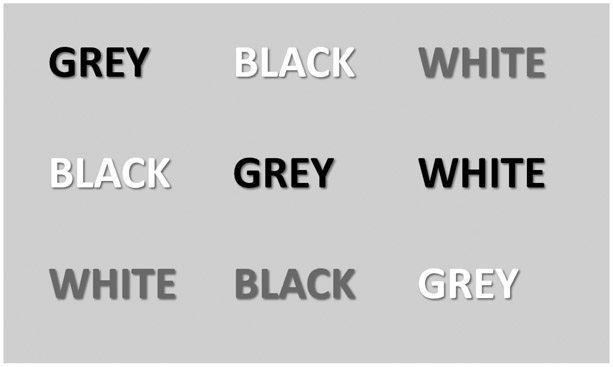

如你所见，这原来相当有挑战性。每当你以为自己做到了的时候，那个词就绝望地朝你大喊：“读我！理解我！”语言对我们来说是如此自然，以至于极难忽视它，这大概是因为我们太习惯它了。

As you see, that turns out to be quite a challenge. Each time you think you manage, the word in question yells at you in despair: “Read me! Comprehend me!” Language comes so natural to us that it is extremely difficult to ignore it, probably because we are so used to it.

那么是什么决定了一个词的理解呢？在可能决定词语加工的若干候选因素中，词频是绝对的赢家。*apple*这个词加工得就是比*unintelligibility*（难以理解）这样的词快，因为*apple*这个词在语言中出现得更频繁。频率的问题在于，尽管它是预测词语加工速度的最佳指标，但它也是许多其他候选因素的替代指标。其中一个候选因素是词长。较短的词往往更频繁（或者说频繁的词往往更短）。<sup>12</sup>当我们考虑*time, year, way, day, thing*和*man*这样较短的名词，以及*say*、*get*、*make*、*go*、*know*这样较短的动词时，我们加工它们的速度比*mispronunciation*、*acknowledgment*、*procrastination*和*professionalism*这样较长的名词，或*authenticate*、*counterbalance*和*recapitulate*这样较长的动词快得多。而后者的频率也远低于前者。

What then determines the comprehension of a word? Among several candidates that could determine word processing, the frequency of a word is the absolute winner. The word *apple* is simply processed faster than a word like *unintelligibility*, because the word *apple* occurs more frequently in language. The problem with frequency is that, though it is the best predictor for the speed of word processing, it is also a proxy for a number of alternative candidates. One such candidate is word length. Shorter words tend to be more frequent (or frequent words tend to be shorter).<sup>12</sup> When we consider shorter nouns like *time, year, way, day, thing*, and *man* and shorter verbs like *say*, *get*, *make*, *go*, *know*, we process them considerably faster than longer nouns like *mispronunciation*, *acknowledgment*, *procrastination*, and *professionalism* or longer verbs like *authenticate*, *counterbalance*, and *recapitulate*. And the latter are far less frequent than the former.

加工得更快的还有像*apple*和*orange*这样的具体词，至少与*freedom*（自由）和*unintelligibility*这样的抽象词相比是如此。如果进行一项评分测试，让参与者评估一个词有多具体或多抽象，得到的评分将能很好地估计理解一个词有多容易。然而，问题在于具体词也比抽象词短，所以决定它们加工速度的也许不是具体性，而是词长——或者是词频，因为我们知道较短的词往往更频繁。

Also processed faster are concrete words like *apple* and *orange*, at least when compared to abstract words like *freedom* and *unintelligibility*. If a rating test were conducted in which participants were asked how concrete or abstract a word was, the resulting ratings would provide a decent estimate of how easy it is to comprehend a word. The problem, however, is that concrete words are also shorter than abstract words, so perhaps it is not so much the concreteness that determines the speed at which they are processed, but the word length—or the word frequency, as we know that shorter words tend to be more frequent.

在较小年龄习得的词加工得也更快。如果把幼儿使用的词列一张表，把成年人使用的词列一张表，那么一个词的习得年龄就能很好地预测这个词被理解的速度。像*ball*（球）这样的词，儿童习得得比*philosophy*（哲学）这样的词早得多。但*philosophy*也比*ball*更抽象。而且这个词更长。频率也更低。

Those words that are acquired at a younger age are also processed faster. If one were to make a list of the words that young children use and a list of the words adults use, the age of acquisition of a word is a good predictor of how fast the word is comprehended. A word like *ball* children acquire much earlier than a word like *philosophy*. But *philosophy* is also more abstract than *ball*. And the word is longer. And is less frequent.

一个词的意义是某个类别的成员还是类别本身，也决定了它的加工速度。像*dog*这样的类别词，比狗这个类别的成员，如*Golden Retriever*（金毛寻回犬）或*Pitbull Terrier*（比特犬），加工得更快。但同样，类别的成员往往也更具体，往往更长，往往频率更高。

Whether the meaning of a word is a member of a category or the category itself also determines the speed with which it is processed. Category words like *dog* are processed faster than members of the category dog, like *Golden Retriever* or *Pitbull Terrier*. But again, the members of the category also tend to be more concrete, and tend to be longer, and tend to be more frequent.

此外，不同类别的词加工得有快有慢。有生命的词（*dog*、*cat*、*woman*）往往比无生命的词（*kitchen*、*freedom*、*lake*）加工得更快。但一个词的有生性也可能由这个词的具体性来解释，而具体性又可能由词长来解释，词长又可能由词频来解释。

Moreover, different categories of words are processed faster or slower. Animate words (*dog*, *cat*, *woman*) tend to be processed faster than inanimate words (*kitchen*, *freedom*, *lake*). But the animacy of a word might also be explained by the concreteness of the word, which in turn might be explained by the length of the word, which in turn might be explained by the frequency of the word.

让我们总结一下。我们理解词比理解非词快，理解看起来和听起来相同的词比理解看起来或听起来不同的词快，理解较早习得的词比理解较晚习得的词快，理解符合句法结构的词比理解不符合的词快，理解具体词比理解抽象词快，理解类别词比理解成员词快，理解有生命的词比理解无生命的词快，理解意义相近的词比理解意义不同的词快，理解较短的词比理解较长的词快。而所有这些效应似乎都有一个共同点，那就是*频率*。被快速识别的词往往是短的、较早习得的、具体的、有生命的、有意义的……而且频率更高。

Let’s summarize. We understand words faster than nonwords, words that look and sound the same faster than words that look or sound dissimilar, words that are acquired earlier faster than words acquired later, words that fit a syntactic construction faster than words that don’t, concrete words faster than abstract words, category words faster than member words, animate words faster than inanimate words, words that are similar in meaning faster than words that are dissimilar in meaning, shorter words faster than longer words. And what these effects all seem to have in common is *frequency*. Words that are recognized fast tend to be short, acquired earlier, concrete, animate, meaningful . . . and more frequent.

那么频率到底怎么回事？显然，你遇到得更多的东西频率更高。频繁的词也更有可能在各种情境中被使用。看起来，如果我们更多地看到、听到、感受到、闻到或尝到某些物体，我们就倾向于在语言中更多地使用它们。这些更有可能是具体的、有生命的物体，更多是基本类别而不是类别的成员。这些很可能也是儿童最先习得的物体，因而也是最先习得的词。这是帮助我们把那些词记在心里的各方面之间相互依存的关系。

So what is it about frequency? Obviously, things you encounter more are more frequent. Frequent words also have a higher likelihood of being used in a variety of situations. It seems that if we see, hear, feel, smell, or taste objects more, we tend to use them more in language. Those are more likely to be objects that are concrete and animate, and are basic categories more than members of a category. And these are probably also the objects and therefore the words that children acquire first. An interdependency of relations between aspects that help us keep those words in mind.

现在，我们可以计算决定孤立词语理解的因素，就像我们对频率、词长、具体性、习得年龄和类别成员身份所做的那样。但这限制了我们能够评估的因素。例如，想象我们想研究一个词的声音或语法类别是否对理解有影响。为了确定什么影响一个词的加工，使用两个词常常是有用的。如果因为第一个词而使第二个词读得更快，就认为这两个词有某种关系。第一个词启动了第二个词。从这些实验中我们知道，如果你读到两个看起来很像的词（*cough*和*dough*），第一个词会启动第二个词。如果两个词看起来不像但听起来像（*tribe*和*tripe*），第一个词同样会启动第二个词。如果词语共享意义（*intelligent, unintelligent*、*intelligible*、*intelligibility*），这些词也会相互启动，即使它们看起来或听起来不像（*buy*和*bought*）。如果两个词构成合乎语法的句法组合（*angry*和*cup*），形容词会启动后面的词（但对于*anger*和*cup*这样的两个名词则没有发现这种效应）。<sup>13</sup>

Now, we can compute the factors that determine the comprehension of words in isolation, as we did for frequency, word length, concreteness, age of acquisition, and category membership. But that limits us in the factors we can evaluate. For instance, imagine that we want to investigate whether the sound of a word has an effect on comprehension, or the grammatical category. To determine what affects the processing of a word, it is often useful to use two words. If the second word is read faster because of the first word, it is assumed that the two words have some relation. The first word primes the second word. From these experiments, we know that if you read two words that look like each other (*cough* and *dough*) the first word primes the second word. If two words do not look but sound like each other (*tribe* and *tripe*), again, the first word primes the second word. If words share meaning (*intelligent, unintelligent*, *intelligible*, *intelligibility*), the words also prime one another, also when they do not look or sound like each other (*buy* and *bought*). If two words make a grammatical syntactic combination (*angry* and *cup*), the adjective primes the sound (but the effect is not found for two nouns like *anger* and *cup*).<sup>13</sup>

所以我们心理词典的组织是复杂的。它不仅基于字母，还基于声音，以及句法和意义。当我们读到两个意义相似的词时，这两个词会相互启动。*coffee*（咖啡）这个词会启动*tea*（茶），但不会启动*dog*。<sup>14</sup>即使对说多种语言的人也是如此。如果你既说法语又说英语，当你读到*dog*时*cat*会加工得更快，而当你看到*dog*的法语对应词*chien*时也是如此。<sup>15</sup>如果这些不同方面都影响一个词的理解，就说明“在按字母顺序组织的心理词典中简单查找”这一比喻是相当成问题的。

So the organization of our mental dictionary is complex. It is based not only on letters but also on sounds, as well as on syntax and on meaning. When we read two words that have a similarity in meaning, the words prime one another. The word *coffee* primes the word *tea*, but it does not prime the word *dog*.<sup>14</sup> This is even true for people who speak multiple languages. If you speak both French and English, *cat* is processed faster when you read *dog* but also when you see the French equivalent for *dog*, *chien*.<sup>15</sup> If these various aspects affect the comprehension of a word, it demonstrates that the metaphor of simply looking up in an alphabetically organized mental dictionary is rather problematic.

## 它很快

## IT’S FAST

我们读一个词平均需要240毫秒。如果240毫秒听起来不算快，那么想象一下。如果我们中的任何人看到屏幕上有一个我们知道会变成红色的绿色圆圈，并被要求在绿圈变红时尽快按下键盘上的任意一个键，我们是无法快于大约240毫秒做到这一点的。<sup>16</sup>所以在这种情况下，我们只需要对一个简单的刺激（从绿到红的变化）作出反应，而且我们确切地知道会出现什么（红色）。而这个简单的任务需要240毫秒。在这个简单的任务中，要对呈现的每一个刺激都保持240毫秒的反应时间是很难的。大约一百个项目之后，我们就会开始表现出疲劳。但在我们听言语或读语言时却不是这样。在你此刻所做的事情中，你毫不费力地从一个词扫向另一个词并获取其意义，仅在本章中你就已经这样处理了两千多个词。

We read a word on average in 240 milliseconds. If 240 milliseconds do not sound that fast, imagine this. If any of us were presented with a green circle on a screen that we know will turn red, and we are asked to press any button on our keyboard as quickly as possible when the green circle turns red, we would not be able to do this faster than approximately 240 milliseconds.<sup>16</sup> So in this situation, we only need to respond to one simple stimulus (a change from green to red), and we know exactly what to expect (red). And that simple task takes us 240 milliseconds. In that simple task, it will be difficult to keep up with the 240 milliseconds response time for each stimulus that gets presented. After a hundred items or so, we will start showing some fatigue. But not so when we are listening to speech or reading language. In what you are doing right now, it takes no effort to glance from word to word and access its meaning, as you have done for over two thousand words already in this chapter alone.

我们如何测量自己理解一个词有多快？科学家们过去使用速示器，这是一种能在指定时间内呈现一个词的设备。<sup>17</sup>如今更常见的是，科学家使用让参与者自己来判断的阅读时间技术。他们在屏幕上向参与者呈现一个词，要求他们尽快判断这个词是不是一个真实的词。或者他们要求参与者说出他们看到的词。按键是获取我们读一个词时所涉及的认知过程信息的一种简便方法。

How do we measure how quickly we understand a word? Scientists used to use tachistoscopes, a piece of equipment that presents a word for a specified amount of time.<sup>17</sup> More commonly now, scientists use reading time techniques that let the participant be the judge. They present participants with a word on a screen and ask them to judge as quickly as possible whether a word is an actual word or not. Or they ask participants to name the word they see. Button presses are an easy way of obtaining information about the cognitive processes involved when we read a word.

一种能提供更详细信息的更精密的方法是使用眼动追踪技术。多年来，眼动仪有过许多不同的类型。有的眼动仪是在隐形眼镜上粘上导线，以监测最细微的运动。也有一些眼动仪的侵入性要小得多。在许多眼动仪中，一小束红外光被投射到眼睛上，并记录其反射。这样你眼睛运动的任何变化都会被捕捉到。早期，参与者被要求把前额抵在眼动追踪系统上，咬住一根咬合棒以保持头部稳定，然后“自然地”阅读一段文本。更现代的眼动仪静静地放在桌子上，你只需要从电脑屏幕上阅读，眼动就会像网络摄像头那样从远处被记录下来。在我看来，与特制的隐形眼镜和咬合棒相比，这样的阅读要自然得多。

A more sophisticated way that provides more detailed information is by using eye tracking technologies. Over the years, eye trackers have been around in many different types. There are eye trackers with contact lenses with wires glued on that monitor the minutest movement. There are also eye trackers that are far less intrusive. In many eye trackers, a small beam of infrared light is projected onto the eye, and the reflection is recorded. Any changes in the movement of your eyes are thus captured. In the early days, participants were asked to put their forehead against the eye-tracking system, clench their teeth on a bite bar to keep their head stable, and then read a text “naturally.” More modern eye trackers sit still on a table, and all you need to do is read from a computer screen while the eye movements are recorded from a distance in a webcam fashion. When compared to specially prepared contact lenses and bite bars, this results in more natural reading if you ask me.

眼动追踪技术告诉我们，每当我们注视一个词时，我们的眼睛会在一个词上停留几百毫秒。在这短暂的注视时间里，眼睛捕捉到大约七到九个字符——而且不是每个词的字符，而是某些词的字符。例如，我们常常不注视*the*、*is*或*and*这样的语法词，而是以某种方式把这些词视为理所当然。我们确实会注视大多数实词，但时间不长。事实上，我们的眼睛根本不会在一个特定的点上注视太久。或者更确切地说，它们做不到。非常短暂的、跳跃式的眼动，即所谓的“眼跳”（saccades），帮助我们从一个注视点跳到下一个注视点。这些眼跳持续大约十到三十毫秒，因此太快了，我们无法从页面上获取任何视觉信息，除非是非常模糊的信息。<sup>18</sup>眼跳似乎大约跳过十个字母，向前移到接下来的内容，但也会向后移。虽然大多数眼动是向前的，但大约10–15%的眼动是向后的，<sup>19</sup>仿佛它们试图把一个已经读过的词重新带回记忆中。但我们通常不会注意到这些向后或向前的移动。

Eye-tracking techniques tell us that whenever we fixate on a word, our eyes come to a rest on a word for a few hundred milliseconds. During this brief fixation time, the eyes capture some seven to nine characters—and not the characters of every word, but the characters of some words. For instance, we often do not fixate on grammatical words like *the*, *is*, or *and*, but we somehow take these words for granted. We do fixate on most of the content words, but not for long. In fact, our eyes don’t fixate on a particular spot for too long at all. Or rather, they can’t. Very brief jerky eye movements, so-called “saccades,” help us to jump from one fixation to the next. These saccades last some ten to thirty milliseconds and are therefore too fast for us to pick up any visual information from the page, unless it is very blurry information.<sup>18</sup> The saccadic eye movements seem to jump approximately ten letters and move forward to what comes next, but also backward. Whereas the majority of eye movements move forward, some 10–15 percent of our eye movements move backward,<sup>19</sup> as if they try to bring a word that we already read back into memory. But we typically do not notice these backward or forward moves.

平均而言，我们每秒读三到六个词，每分钟大约两百到四百个词。但这取决于多种因素：文本的呈现方式、字体和颜色，以及读者的阅读技能。它也取决于文本的体裁。我最好的猜测是，在本书中你注视每个词大约需要220毫秒，但与本书相比，一篇浅显的叙事文本可能每个词为你节省大约二十毫秒，而一篇物理或生物文本可能每个词让你多花大约四十毫秒。所以，如果你跳过所有的咖啡或洗手间休息，继续读这里呈现给你的词，你应该能在大约七个小时内读完这本书。继续读吧！

On average, we read some three to six words per second, some two hundred to four hundred words per minute. But this depends on a variety of factors: the presentation of the text, its font and color, and the reading skills of a reader. It also depends on the text genre. My best guess is that it takes approximately 220 milliseconds per word you fixate on in the current book, but compared to this book, an easy narrative text might save you some twenty milliseconds per word, while a physics or biology text may cost you some forty milliseconds extra per word. So if you skip all coffee or bathroom breaks, and continue reading the words presented to you here, you should be able finish this book in approximately seven hours. Just keep on reading!

在对一个词的一次眼睛注视中，我们获取了多少信息？这是一个很难回答的问题，因为它取决于我们能从注视点的左右两侧获取多少信息。取决于眼睛能聚焦的部分——中央凹区域——摄入多少，以及中央凹周围的区域——副中央凹和周边——摄入多少。认知心理学家基思·雷纳和乔治·麦康基——以其开创性的眼动追踪研究而闻名——想出了一个巧妙的办法来确定知觉广度。他们让人们注视的词随注视而变化。当某人看一个词时，其他的词会改变，而当这个人移到其他词上时，那个词又会改变。现在，如果雷纳和麦康基把其他的词改成*x*，而人们没有注意到这些*x*，那么未改变的词就在知觉广度之内。反之，如果一个词变成了*x*而参与者注意到了这一变化，它就超出了知觉广度。在一项研究中，他们发现读者使用的是从注视点起十到十一个字符位置。这基本上意味着读者一次看到的不超过两到三个短词。较长的词无法一次看全！尽管当你看一个词时，你相当确信其他词是什么，但随注视变化的研究表明，你并不能确信。如果这些词变成了*x*（如果它们在你所聚焦之处十到十一个位置之外），你根本不会注意到！<sup>20</sup>

How much information do we pick up during an eye fixation on a word? This is a difficult question to answer, because it depends on how much information we can get on the left and the right of the point of the word. How much the part of the eye that can focus—the foveal area—takes in, and how much the areas around the fovea take in, the parafoveal and the periphery. Cognitive psychologists Keith Rayner and George McConkie—best known for their groundbreaking eye-tracking research—came up with a clever solution to identify the perceptual scan. They made the words people looked at gaze contingent. When somebody looked at a word, the other words changed, and when the person moved to the other words, the one word changed. Now if Rayner and McConkie changed the other words to *x*’s and people did not notice these *x*’s, the unchanged words were part of the perceptual span. If, on the other hand, a word changed to *x*’s and the participant noticed the change, it exceeded the perceptual span. In one study, they found that readers are using ten to eleven positions from the fixation point. This basically means that readers do not see more than two to three short words at a time. Larger words cannot be seen at once! Even though when you look at a word, you are pretty convinced of the nature of the other words, the gaze-contingent studies demonstrate that you cannot be convinced. If these words changed to *x*’s (if they stayed outside the ten to eleven positions away of what you focus on), you wouldn’t notice a thing!<sup>20</sup>

在另一项实验中，雷纳没有用*x*来替换词，而是用形状和字母替代物。例如，参与者读句子：*The king watched the traitor from his throne*（国王从王座上注视着叛徒）。但*traitor*被替换成了*teacher*（老师），它在句法和语义上都是一个不错的替代词。其他替代物是非词：首尾字母正确，其余部分看起来相同（*tcaobcr*）；首尾字母相同，其余部分看起来不同（*tifjrir*）；或者首尾字母以及其余部分都只是看起来相同而实际并不相同（*fcaobcn*）。当读者注视的位置在那串字母开头左侧三到四个字符位置以外时，他们没有认出那串字母不是一个词。但特别引人注目的是，替代词*teacher*被处理得与目标词*traitor*非常相似。很难直观地展示参与者能看到什么，因为呈现方式随眼睛注视而变化，但让我试一试。参与者看到的是句子“The king watched the traitor from his throne.”

In another experiment, Rayner used not *x*’s to replace the word, but shape and letter substitutes. For instance, participants read the sentence: *The king watched the traitor from his throne*. But instead of *traitor*, the word *teacher* was used, which was both syntactically and semantically a good substitute. Other substitutes were nonwords with the first and last letter being correct, and everything else looking the same (*tcaobcr*), the first and the last letter being the same, and everything else not looking the same (*tifjrir*), or the first and the last letter as well as everything else looking but not being the same (*fcaobcn*). Readers did not recognize that a letter string was not a word when they fixated on more than three to four character positions to the left of the beginning of that string. But what was particularly striking is that the substitute word *teacher* was treated very similar as the target word *traitor*. It is difficult to visualize what participants were able to see, because the presentation changed as a function of the eye gaze, but let me give it a try. Participants saw the sentence “The king watched the traitor from his throne.”

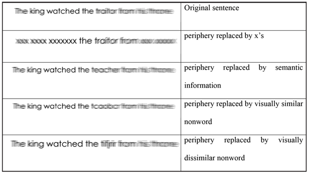

*来源*：Rayner 与 McConkie（1977）。

*Source*: Rayner and McConkie (1977).

当参与者聚焦在*watched*这个词上时，视觉上和语义上的不一致都导致了更长的注视时间，这表明他们所注视的词以外的信息，即他们周边视野中的词，被纳入了考虑。不过，周边信息对于视觉信息限于七到十二个字符，对于语义信息限于一到六个字符。但最有意思的是，语义上相似的词（而不是非词）表现得最像原来的词，仿佛心智在眼睛周边视野的某个地方加工了它本来并不打算加工的信息。

When participants focused on the word *watched*, both visual and semantic inconsistency resulted in higher fixation times, suggesting that information away from the word they fixated on, words in their periphery, was taken into account. However, the peripheral information was limited to seven to twelve characters for visual information and one to six characters for semantic information. But most interestingly, the semantically similar words, but not the nonwords, behaved most like the original word, as if the mind somewhere in the eye’s periphery processed information it had not really intended to.

这些研究的另一个有意思的发现是，知觉广度并不对称。它在注视点右侧延伸得远比左侧多。这种覆盖读者即将读到的更多信息的不对称广度，对于英语（以及荷兰语、德语和法语）读者而言是如此，而对于希伯来语这样从右向左印刷的语言则正好相反。<sup>21</sup>对于中文和日文，无论是横排还是竖排，都发现了非常相似的结果。<sup>22</sup>这些发现表明，心智在阅读时是向前思考的。心智不仅根据视觉信息，而且特别根据句法和语义信息来猜测一个词是什么，而且向前看的多于向后看的。这就是那个有根据的猜谜游戏。

Another interesting finding from these studies is that the perceptual span was not symmetrical. It extended far more to the right of the fixation point than to the left. The asymmetric span covering more of the information that is coming up for readers of English (and Dutch, German, and French) is reversed for languages that are printed from right to left, such as Hebrew.<sup>21</sup> For Chinese and Japanese, very similar results have been found, both for horizontal and for vertical presentation of the letters.<sup>22</sup> What these findings show is that the mind is thinking ahead when reading. The mind is guessing the nature of the word not only on the basis of visual information but also particularly on syntactic and semantic information, and does that with more forward looking than backward looking. The educated guessing game.

让我们再多举例说明一下。首先，当我们把“The quick brown fox jumps over the lazy dog”（敏捷的棕色狐狸跳过了懒狗）这样一个“正常”的句子与“dog lazy the over jumps fox brown quick the”作比较时，句子顺序和词语的语义组织很重要这一证据就显而易见了。但这可能更多地说明了词语在句子中的呈现方式，而不是你预测下一个词之后那个词的能力。因此，让我们做个小实验，你自己来测试一下。下面我列出了一串词。现在拿一张纸盖住最上面一行，然后往下移。你能多好地预测下一个词，也就是说，不注视这个词、不在心理词典中查找它、不获取其意义、然后再移到下一个词？现在反过来试试。把纸从下往上移，看看这如何改变你加工每一个词的方式。我猜从下往上读比从上往下读所需的时间要长得多，而这并不是因为你阅读的方向（对说英语的人来说这本来就不自然，因为我们习惯从左往右读）。

Let’s illustrate this a bit more. First of all, the evidence that the sentence order and the semantic organization of words matter is obvious when we compare a “normal” sentence like “The quick brown fox jumps over the lazy dog” with “dog lazy the over jumps fox brown quick the.” But this may say more about the presentation of words in a sentence than your ability to make predictions on the word that follows the next word. Let’s therefore do a little experiment and test this yourself. Below, I have presented a list of words. Now put a sheet of paper over the top line and move it down. How well would you be able to predict the next word, that is, without fixating on the word, looking it up in your mental dictionary, accessing its meaning, and then moving on to the next word? Now try it the other way around. Move your sheet of paper from the bottom to the top and see how this changes how to process each and every word. My guess is that it takes considerably longer reading from bottom to top than from top to bottom, and not because of the direction you are reading things in (which is unnatural for English speakers anyway, because we tend to read from left to right).

| The | based | rules |
| --- | --- | --- |
| idea | on | is |
| that | a | by |
| a | system | no |
| language | of | means |
| is |  | novel. |

这个例子表明，我们显然不是单独读每个词并查找其意义，而是对我们遇到的词作出预测，这是一种基于我们过去对词频和句子结构的经验而累积起来的预测。<sup>23</sup>这就解释了为什么我们在下面这样的句子上会遇到困难：

What this example shows is that we apparently do not read each word separately and look up its meaning, but we make predictions on the words we encounter, an accumulated prediction based on past experiences we have with the frequency of words and sentence structures.<sup>23</sup> This explains why we struggle with sentences like

> The swimmers drowned in the lake were not found until the next morning.（在湖里被淹死的游泳者直到第二天早上才被找到。）

> The swimmers drowned in the lake were not found until the next morning.

> The general presented copies of the report was aware of the problems.（被呈交了报告副本的将军意识到了这些问题。）

> The general presented copies of the report was aware of the problems.

> The government plans to raise taxes were defeated.（政府提高税收的计划被否决了。）

> The government plans to raise taxes were defeated.

> The investigation revealed the error resulted from gross negligence.（调查表明，这一错误是由严重疏忽造成的。）

> The investigation revealed the error resulted from gross negligence.

这些句子把你引上了一条你熟悉的句法路径（游泳者在湖里淹死了；将军呈交了副本；政府计划提高税收；调查揭示了错误），但突然你在所走的路上被引入歧途，不得不往回走，另选一条新路。这些句子被称为花园路径句，在20世纪70年代，语言学出版物中涌现出大批改行当园丁的语言学家。花园路径研究者试图解释为什么我们会在这些句子的句法结构上绊倒，并在（结果证明是）错误的路径上徘徊。例如，他们定义了一些规则，规定人类偏爱语法复杂度最低的句法结构。或者他们用把输入信息错误地连接到最近加工的信息上来解释这些认知上的绊倒。人们提出了一些有意思的句法理论。但词的意义常常压倒句法结构。下面两个花园路径句的句法结构完全相同，然而你在第二句上的困难无疑要比在第一句上少。<sup>24</sup>

These sentences led you up to a syntactic path you are familiar with (swimmers drowned in the lake; the general presented copies; the government plans to raise taxes; the investigation revealed the error), but suddenly you were led astray on the path you followed, and you had to walk back, taking a new path. These sentences are called garden-path sentences, and in the 1970s, publications in linguistics blossomed with linguists-turned-gardeners. Garden-path researchers tried to explain why we stumble over the syntactic structure of these sentences and wander on (what turns out to be) the wrong path. For instance, they defined rules that stated that humans prefer those syntactic structures that were simplest in their grammatical complexity. Or they explained these cognitive trip-overs by the erroneous linking of the incoming information to the most recently processed information. Some interesting syntactic theories were proposed. But the meaning of words often trumped the syntactic structures. The following two garden-path sentences are identical in syntactic structure, and yet you undoubtedly have less difficulty with the second than with the first one.<sup>24</sup>

> The doctor examined asked the patient about his recovery.（被检查的医生向病人询问了他的康复情况。）

> The doctor examined asked the patient about his recovery.

> The patient examined asked the doctor about his recovery.（被检查的病人向医生询问了他的康复情况。）

> The patient examined asked the doctor about his recovery.

所以，如果我们给上面呈现的句子加一点语境，我们就能作出更好的猜测。例如，如果我们回到关于“在湖里被淹死的游泳者直到第二天早上才被找到”的那条悲伤消息，一点语境就能让我们不再被引入歧途。

So if we add a bit of context to the sentences presented above, we can make better guesses. For instance, if we go back to the sad news about “the swimmers drowned in the lake were not found until the next morning,” a little context allows us to not be led astray anymore.

> 搜救队整夜搜寻在湖中失踪的游泳者。The swimmers drowned in the lake were not found until the next morning.（在湖里被淹死的游泳者直到第二天早上才被找到。）

> The search crew had searched all night for the swimmers that had gone missing in the lake. The swimmers drowned in the lake were not found until the next morning.

这对我们这些语言使用者来说是个好消息。正如我们几乎从不接触孤立的词一样，我们也几乎从不接触孤立的句子。词语和句子通常出现在语境中。前段时间，我和一名研究生对上面那样令人困惑的花园路径句做了一项眼动追踪实验。<sup>25</sup>除了使用原句之外，我们还使用了添加了一些语境的句子，有的是具体语境，有的是整体语境。在所有添加了语境的情况下，我们都能把读者引离花园路径，眼动追踪数据显示，所有最初的困惑基本上都消失了。如果语言在其自然栖息地——语境中——呈现，参与者就不会遇到任何困难。

And that is good news to us, language users. Just like we are hardly ever being presented with words in isolation, we are hardly ever being presented with sentences in isolation. Words and sentences typically appear in context. A while back, I conducted an eye-tracking experiment with a graduate student on confusing garden-path sentences like the ones above.<sup>25</sup> In addition to using the original sentences, we also used sentences with some added context, some specific context, and some overall context. In all cases with context being added we were able to guide the reader off the garden path, with the eye-tracking data showing that all initial confusion was basically gone. Participants did not experience any difficulties if language was presented in its natural habitat, in context.

再举另一个心理语言学实验，它考察人们记住的是句子本身还是句子的意义。<sup>26</sup>参与者在实验说明中读到了下面这个句子。

Or take another psycholinguistic experiment that looked at whether people remembered the sentence itself or the meaning of the sentence.<sup>26</sup> Participants read the following sentence as part of their experiment instructions.

> 给结果打分时，对你的正确答案不要做任何处理，但要仔细标出那些错误的答案。

> When you score the results, do nothing to your correct answer but mark carefully those answers which are wrong.

参与者并不知道他们在参加一项回忆实验。令他们吃惊的是，研究者向他们呈现了这个句子中的片段，问他们是否真的读到过每个片段。例如，一组人被问他们读到的是*your correct*还是*correct your*，而另一组人被问他们读到的是*mark carefully*还是*carefully mark*。两组的区别在于，前一组看到的是意义发生了变化的片段，而另一组看到的是意义没有变化、只有确切措辞变化的片段。意义变化组的正确率为100%，而形式变化（但意义不变）组的表现要差得多，正确率只有50%。<sup>27</sup>我们对句子确切措辞的记忆似乎会消失，而对要点的记忆却会保留。

The participants had no idea they were participating in a recall experiment. To their surprise they were presented with snippets from the sentence and asked whether or not they had actually read each snippet. For instance, they were asked whether they had read *your correct* or *correct your*, while another group was asked whether they had read *mark carefully* or *carefully mark*. The difference between the two groups was that the former group was presented with a change in meaning, whereas the other group was presented a snippet that did not change in meaning, only in the exact wording. The change-in-meaning group scored 100 percent correct, while the change-in-form (but not in meaning) group performed considerably lower, at only 50 percent accuracy.<sup>27</sup> Our memory for the exact wording of a sentence seems to vanish, whereas the memory for the gist remains.

或者在另一项实验中，<sup>28</sup>参与者读了一长串句子，之后被问到他们看到过哪个句子。例如，这一串互不相关的句子中包括*The window is not closed*（窗户没有关）。多项选择测试包括以下四个句子：

Or in yet another experiment,<sup>28</sup> participants read a long series of sentences and were later asked which sentence they had seen. For instance, the series of unrelated sentences included *The window is not closed*. The multiple-choice test included the following four sentences:

> The window is not closed.（窗户没有关。）

> The window is not closed.

> The window is closed.（窗户关着。）

> The window is closed.

> The window is not open.（窗户没有开。）

> The window is not open.

> The window is open.（窗户开着。）

> The window is open.

第一个句子是参与者读过的句子，也许不出所料，那是他们记得最清楚的一句。但当他们出错时，事情就变得有意思了。第二个选项的确切措辞和第三个选项的句法结构最接近参与者之前看到的句子。但大多数人选择了第四个，即意义上最接近的那个句子，而不是措辞或句法结构上最接近的句子。

The first sentence was the sentence participants had read, and perhaps unsurprisingly, that was the one they best remembered. But when they made a mistake, things got interesting. The exact wording of the second multiple-choice answer and the syntactic structure of the third one came closest to what participants had seen before. But most people chose the fourth one, the sentence that was closest in meaning, not closest in wording or syntactic structure.

所以，对语言本身的熟悉程度似乎很重要，正如我们在能从打乱的字母中重建词语这一现象中所看到的。句子的结构似乎很重要，正如我们在花园路径句中所看到的。语境似乎也很重要，正如我们从启动实验的发现以及能够根据句子所处的语境逆转花园路径效应的发现中所看到的。但在所有这些情况下，意义都很重要。

So familiarity with the language itself seems to be important, as we have seen in the scrambled letters from which we are able to reconstruct words. The structure of the sentence seems to be important, as we have seen in the garden-path sentences. And the context seems to be important, as we have seen in the findings from priming experiments and the findings that we can reverse garden-path effects on the basis of the context the sentences are placed in. But in all these cases, meaning matters.

这让我有机会向你介绍语篇心理学的世界。心理学家沃尔特·金奇和他的团队让参与者阅读十八篇短文。读完这些文本后，参与者所要做的只是判断他们是否见过呈现给他们的某个句子。非常简单。然而，给他们看的句子要么直接来自他们看过的文本（复制粘贴），要么是释义（在用词和句子结构上有一些细微差别），要么是推论（可以从某个句子得出、但没有明确陈述的结论）。像“那是美好的一天。琼放下毛巾，在阳光下晒了半个小时”这样的小短文，会有对第一句的释义，如“她铺开了毛巾”，以及对第二句的推论，如“她躺在了毛巾上”。当参与者在读完文本后立即接受测试时，他们记得最清楚的是原句，其次是释义，并且说他们没有见过推论句。四十分钟后，原句与释义之间的差别基本消失了。两天后，参与者几乎无法区分原句、释义和推论句。<sup>29</sup>正是对语言、句子结构和语言语境的熟悉帮助我们进行猜谜游戏。

This gives me the opportunity to introduce you to the world of discourse psychology. Psychologist Walter Kintsch and his team asked participants to read eighteen short texts. After reading these texts, all participants had to do was to identify whether they had seen a sentence presented to them or not. Pretty simple. However, the sentences they were shown either came directly from the text they had seen (copied and pasted), were paraphrases (with some minor word choice and sentence structure differences), or were inferences (possible conclusions drawn from a sentence but not explicitly stated). A mini-text like “It was a wonderful day. Joan put down her towel and baked in the sun for half an hour” would have a paraphrase of the first sentence, as in “She spread out her towel,” and an inference of the second sentence, as in “She lay down on her towel.” When participants were tested immediately after having read the texts, they best remembered the original sentences, followed by the paraphrases, and said they had not seen the inference sentences. After forty minutes, the differences between original sentence and paraphrase was basically gone. And after two days, participants could hardly distinguish between the original, the paraphrase, or the inference sentences.<sup>29</sup> It is the familiarity with the language, the sentence structure, and the linguistic context that help us in our guessing game.

但看起来，甚至背景信息也有助于我们猜测。昨晚我和妻子去了附近的一家餐馆。我们等着被领位，服务员来了以后，我报了预订的名字，友好的服务员把我们领到了桌前。我们点了饮料，然后看菜单。很难作出选择，但我们还是点了开胃菜和主菜。真是一顿美妙的晚餐。之后我们点了一份甜点：巧克力软糖。服务员拿来了我们的外套，礼貌地为我们开着门。回到车上时，我们发现挡风玻璃结冰了，不得不刮掉那层薄冰。

But it even seems to be the case that background information helps us in our guessing. Last night my wife and I went to a nearby restaurant. We waited to be seated, and when the waiter arrived, I gave the reservation name, and the friendly waiter guided us to our table. We ordered drinks and then looked on the menu. It was difficult to make a choice, but we ordered our appetizer and entrée. A wonderful dinner indeed. Afterward, we ordered a dessert: chocolate fudge. The waiter got our coats and gently held the door open for us. When we got back to our car, we noticed that the windshield was frozen, and we had to scrape off the thin layer of ice.

我打赌你并没有对我非常不满。你为什么要不满呢？我刚刚告诉了你我昨晚的经历，而你并没有因为我没付账而对我非常不满。我们当然付了账（还加了小费），但这基本上是我们所有人心中都有的餐馆脚本的一部分，这个脚本包括——即使没有明确提到——付账。你只是根据你心中显然有的餐馆脚本填补了空白。<sup>30</sup>对于许多场景，我们已经预料到接下来会发生什么。或者我们知道有哪些物体和物品在场。如果我在故事中提到服务员拿着开瓶器来到我们桌前，你几乎不会注意到它。但如果服务员拿着螺丝刀来到我们桌前，你可能会感到惊讶。类似地，如果我告诉你我走进餐馆，点了甜点，被领到桌前，等着被领位，这个故事几乎是不合语法的（当然，除非你一扫而过这个例子，作了一些有根据的猜测，甚至没有注意到它的不合语法）。

I bet you are not deeply upset with me. Why would you? I just told you about my evening last night, and you are not deeply upset with me for not having paid the bill. Of course we paid the bill (and added a tip), but it is basically part of a restaurant script we all have in our minds, which includes—even if is not explicitly mentioned—paying the bill. You just filled in the blanks on the basis of a restaurant script that you apparently have in mind.<sup>30</sup> For many scenarios, we already anticipate what is going to happen next. Or we know what objects and items are present. If in my story I had mentioned that the waiter arrived at our table with a corkscrew, you would have hardly paid attention to it. But if the waiter arrived at our table with a screwdriver, you might be surprised. Similarly, if I had told you that I entered the restaurant, ordered the dessert, was guided to the table, and waited to be seated, the story is almost ungrammatical (unless of course you glanced over this example, made some educated guesses, and didn’t even get the ungrammaticality).

科学家们认为，就像我们在学校里熟悉的句子语法一样，也存在着某种类似故事语法的东西。弗拉基米尔·普罗普在二十世纪初研究了俄罗斯童话的故事结构。他发现这些故事有一个模式。它通常以一种世界上什么都不会出错的一般情境开始。一位王后和一位国王，他们有一个女儿，一切都很好。突然发生了一些事情。一个女巫出现了，一条龙破坏了平静安宁的生活，或者某个别的反派填补了邪恶轴心的位置。例如，公主可能被绑架了。然后故事中出现某种高潮。英雄（刻板地说，是男性王子）出现了，与龙战斗。当一切几乎都要失去时，英雄还是赢了。在高潮冲突解决之后，情况恢复正常，或者变得更好，每个人从此过上了幸福的生活（王子和公主显然结了婚）。

Scientists have argued that like the grammar of a sentence we are all familiar with from school, there is also something like a story grammar. Vladimir Propp, in the early part of the twentieth century, studied the story structure of Russian fairy tales. He found out that there is a pattern to these stories. It commonly starts with a general situation where nothing in the world could go wrong. A queen and a king, who have a daughter, and all is well. Suddenly something happens. A witch shows up, a dragon is ruining the peaceful and quiet life, or some other villain fits the axis of evil. For instance, the princess might get kidnapped. Then there is some climax in the story. The hero (stereotypically the male prince) shows up and fights a dragon. When everything almost seems to be lost, the hero wins nevertheless. And after the resolution of the climactic conflict, the situation gets back to normal, or gets even better, with everybody living happily ever after (and the prince and princess obviously getting married).

如果这听起来太像童话，那么随便拿一部詹姆斯·邦德电影、任何一部迪士尼电影、任何一部《哈利·波特》《魔戒》或《星球大战》电影，你都会找到这些故事语法的证据。显然，你在它们的原著中也会找到。如果詹姆斯、艾莎、哈利、弗罗多或卢克输掉了战斗，读者或观众离开电影院时会相当不满。他们可能几乎要输了，但我们预期会有一个幸福的结局，以及一些波折，否则电影就不够激动人心了。

If this sounds too much like a fairy tale, take any James Bond movie, any Disney movie, any Harry Potter, Lord of the Rings, or Star Wars movie, and you will find evidence for these story grammars. Obviously, you will also find them in their original books. The reader or moviegoer would leave the cinema rather disgruntled if James, Elsa, Harry, Frodo, or Luke lost the battle. They may almost lose it, but we anticipate a happy ending, and some disruption, otherwise the movie would not be exciting enough.

这与把那些词记在心里有什么关系呢？嗯，让我们回顾一下。我们从词优效应开始，语言使用者不是通过把单个字母串联起来构成词，而是根据一个词的部分字母来猜测这个词。然后我们转向句子，句子不是作为词的串联被理解的，也涉及估猜。类似地，我们对文本、故事和语篇中的故事线进行估猜，因为我们不只是读句子的串联。

What does this have to do with keeping those words in mind? Well, let’s recap. We started out with a word-superiority effect with language users making words not out of a concatenation of individual letters, but guessing the word on the basis of some of its letters. We then moved onto sentences, which are not understood as a concatenation of words, but involve guesti-mates too. Similarly, we guestimate the story line in texts, stories, and discourse, as we don’t just read the concatenation of sentences.

所以本章一开始的观点是，阅读过程大致如下：“阅读是一个精确的过程。它涉及对字母、词语、拼写模式和较大语言单位的准确、详细、按顺序的知觉和识别。”但我们基本上最终得出的是：“阅读是一个选择性的过程。它涉及部分地利用根据读者的预期从知觉输入中选取的、现有的最少语言线索。随着这些部分信息被加工，会作出一些试探性的决定，并随着阅读的进行被证实、否定或修正。”语言加工是一场（有根据的）猜谜游戏。<sup>31</sup>

So we started out this chapter with the idea that the reading process is something like the following: “Reading is a precise process. It involves exact, detailed, sequential perception and identification of letters, words, spelling patterns, and large language units.” But we basically ended up with “Reading is a selective process. It involves partial use of available minimal language cues selected from perceptual input on the basis of the reader’s expectation. As this partial information is processed, tentative decisions are made to be confirmed, rejected, or refined as reading progresses.” Language processing is a(n educated) guessing game.<sup>31</sup>

## 听

## LISTENING

名为阅读的猜谜游戏是困难的。大多数儿童在六岁之前都没有掌握阅读。难怪，白色背景上那些弯弯曲曲的形状需要被转换成有意义的信息。然而阅读可以利用一些听者所没有的信息。至少一页上的字母形状是成簇的。字母序列被空格、逗号、句号或其他标点符号与其他序列很好地分隔开来。在阅读中，一个词何时结束、另一个词何时开始是清楚的——词与词之间的空格一路引导着你。一个句子何时结束、下一个句子何时开始也是清楚的——标点符号和大写字母会告诉你。而且读者按自己的节奏阅读。如果读得太快，她可以放慢速度。如果读得太慢（或内容太无聊），她可以加快速度。如果阅读变得复杂，读者可以回头重读一些词或整个段落。

The guessing game called reading is difficult. Most children have not captured reading before they turn six. No wonder, with the wiggly shapes on a white background that need to be translated to sensible information. Yet reading can take advantage of a number of pieces of information that hearers do not have. At least the shapes of the letters on a page are clustered. Sequences of letters are nicely separated from other sequences with a space, a comma, a period, or other punctuation markers. In reading, it is clear when one word stops and another word starts—the spaces between words guide you along the way. It is also clear when one sentence stops and the next one starts—punctuation markers and capitals will tell you. And the reader reads at her own pace. If the reading goes too fast, she can slow down. If the reading is too slow (or the content too boring), she can speed up. If the reading becomes complex, the reader can go back and reread words or entire sections.

另一方面，听者可以依据的东西要少得多。她的猜测工作相当了不起。在言语中，词语之间没有明显的停顿分隔，而是在一股连续的气流中交织在一起，使人难以确定它们何时开始、何时结束。句子没有用标点符号或大写字母标出，使人难以确定一个句子何时结束、新的句子何时开始。如果你跟丢了词和句子，也没有机会回到已经说过的内容上。没有机会回视前面的词，更不用说回到前一阵子说过的内容了。听者完全依赖于说话者此时此地提供给她的东西。

The hearer, on the other hand, has considerably less to work from. Her guessing work is rather amazing. In speech, words are not separated by distinct pauses but are laced together in one continuous airstream, making it difficult to determine when they start and when they end. Sentences are not marked by punctuation markers or capitals, making it difficult to determine when a sentence has ended and when a new sentence has started. And if you had lost track of words and sentences, there is no opportunity to go back to what has been said. There is no opportunity for regressions to previous words, let alone to what was said a while back. The hearer is fully dependent on what the speaker provides to her right here, right now.

而即使是说话者所说的东西也很难。想象听到*ball*、*bill*、*able*和*rob*这几个词。这四个词中的*b*听起来都略有不同。作为语言使用者，你怎么知道它们属于同一个音，即*b*呢？更糟的是，即使你已经知道这四个词中的*b*音略有不同，这些音在语境中还会发生变化。当你大声读出*I rob burglars*（我抢劫窃贼）、*I rob plenty of people*（我抢劫很多人）、*I rob ten people*（我抢劫十个人），或者最政治正确的*I rob nobody*（我谁也不抢）时，人们假设*rob*这个词是同一个，但在所有四个例子中，*rob*这个词的最后一个音的发音都不同。然而大多数人毫不费力就能把*rob*这个词声音上的这些细微变化归回到同一个词上（然后报警）。

And even what the speaker says is difficult. Imagine hearing the words *ball*, *bill*, *able*, and *rob*. The *b*’s in all four words sound slightly different. How would you know as a language user that they belong to the same sound, the *b*? And to make matters worse, even if you had learned that the four words have slightly different *b* sounds, these sounds change when placed in context. When you read out loud *I rob burglars*, *I rob plenty of people*, *I rob ten people*, or the most politically correct *I rob nobody*, the assumption is that the word *rob* is the same, but in all four examples, the last sound of the word *rob* is pronounced differently. Yet most people have little difficulty bringing back the small variations of the sound of the word *rob* to the same word (and call the police).

说到警察，在语言学中把听的过程等同于读的过程是一种罪过。我们刚刚看到，阅读语言与听言语之间存在重要的差别。尽管人们可以认为听言语更自然——儿童会自动学会交流，但学习阅读要困难得多——研究阅读过程却更容易，理解其中发生的事情也更方便。像眼动仪或按键这样的设备为测量发生了什么提供了简便的工具，而且由于在阅读中——而在听中不太是这样——参与者完全控制自己读多快、是想往前跳还是往回跳，关于阅读的实验文献就是比关于听语言的多。而且，在阅读词语中发现的许多效应也适用于听词语。例如，与书面语一样，在言语中似乎也存在词优效应，音位在词中比在非词中被更快地察觉。<sup>32</sup>而且与书面语一样，在言语中，我们在通读一个句子时会考虑候选词，如果词中有“打字错误”也会重建它们。

Talking about police, it is a crime in linguistics to equate the hearing process with the reading process. We have just seen that there are important differences between reading language and hearing speech. Even though one can consider hearing speech to be more natural—children automatically learn how to communicate, but they have a much harder time learning to read—it is easier to study the reading process and more convenient to understand what’s going on. Equipment like eye trackers or button-press options provide easy tools to measure what’s going on, and because in reading—and less so in listening—the participant has full control on how fast she reads, whether she wants to jump forward or jump back, there simply is more experimental literature on reading than on hearing language. And many of the effects that have been found for reading words apply to hearing words. For instance, as in written language, in speech there seems to be a word superiority effect with phonemes being detected more quickly in words than nonwords.<sup>32</sup> And as in written language, in speech we consider word candidates when reading through a sentence, and reconstruct words if they contain a typo.

在心理语言学家迈克·塔嫩豪斯及其团队的一项实验中，参与者看着四幅图片：一幅化学课上用的杯子的图片，一幅昆虫的图片，一幅扬声器的图片，以及一幅马车的图片。<sup>33</sup>你猜对了，是烧杯（beaker）、甲虫（beetle）、扬声器（speaker）和马车（carriage）。他们向参与者呈现*beaker*这个词，同时记录参与者的眼睛注视。基本上，实验者想确定意义（图片）的激活是基于这个词的声音还是基于这个词的韵脚。在参与者听到*beaker*这个词被念出后的最初200毫秒内，注视按比例同样地落在所有图片上。但在200毫秒左右，可以观察到一个变化。不相关的词*carriage*在注视竞赛中落败了。它没有被看，所有注意力都转向了另外三幅图片。甲虫和烧杯都得到了相当多的注视。扬声器仍在竞赛中，但输给了甲虫和烧杯，而且不出所料，400毫秒之后，谁赢得了注视竞赛就很明显了：烧杯。

In an experiment by psycholinguist Mike Tanenhaus and his team, participants looked at four pictures: a picture of a cup used in chemistry classes, a picture of an insect, a picture of a loudspeaker, and a picture of a carriage.<sup>33</sup> You guessed it, that of a beaker, beetle, speaker, and carriage. They presented participants with the word *beaker*, while the eye gaze of the participants was recorded. Basically, the experimenters wanted to determine whether the activation of the meaning (the picture) was based on the sound of the word or the rhyme of the word. In the first 200 milliseconds after participants heard the word *beaker* being pronounced, the fixations hit all the pictures proportionally the same. But around 200 milliseconds, a change could be observed. The unrelated word *carriage* lost in the fixation race. It was not looked at, and all attention went to the other three pictures. Beetle and beaker both got quite some fixations. Speaker was still in the race but was losing out to beetle and beaker, and unsurprisingly, after 400 milliseconds, it became obvious who won the fixation race: beaker.

这个实验表明，一个词开头的音系信息会激活若干读音相似的候选词，但也会激活那些不是开头、而是结尾读音相似的候选词。用我们心理词典的例子来说，显然我们不仅查看心理词典的*B*部分，寻找开头读音相同的其他候选词，而且也会（尽管很短暂地）查看-*EAKER*部分，寻找词尾读音相似的候选词。

This experiment showed that phonological information at the start of the word activates several candidates with similar sounds, but also candidates for which the sound is similar not at the start but at the end of the word. Translated to our mental dictionary example, apparently we do not only look at the *B*-section of the mental dictionary because other candidates whose beginning sound the same, but also, albeit briefly, at the -*EAKER* section for candidates that have a similar word-sound ending.

所以显然语言加工是渐进的：当我们听到一个词时，我们会立即对与输入信息相匹配的潜在候选词作出有根据的猜测。读音相似的词不会被完全排除在猜测的候选之外，甚至有语义联想的词也是候选词。我们根据先前的观察形成多个假设。

So apparently language processing is incremental: when we hear a word, we immediately make educated guesses about potential candidates that match the incoming information. Words that sound similar are not entirely ruled out as candidates for the guessing, and even words that have semantic associations are candidates. We form multiple hypotheses based on our prior observations.

而且我们形成有根据的猜测的速度很快。在一项类似于烧杯实验的实验中，参与者听到*hammer*（锤子）这个词，看着屏幕上呈现的锤子图片，但他们也看了钉子的图片。而当他们听到*hammock*（吊床）时，同样的事情也发生了。甚至*hammock*也让我们作出有根据的猜测，以为参与者真正听到的是与*nail*（钉子）有关的词。类似地，当参与者听到与*lock*（锁）和*logs*（原木）前两个音位相似的声音时，他们也急于去看*key*（钥匙）和*wood*（木头）（但不看*deer*或*apple*）。<sup>34</sup>

And we form our educated guesses quickly. In an experiment similar to the beaker experiment, participants heard the word *hammer* and looked at the picture of a hammer presented on the screen, but they also looked at the picture of a nail. And when they heard the word *hammock* the same happened. Even *hammock* made us make an educated guess that what participants really heard was *nail*. Similarly, when participants heard something similar to the first two phonemes of *lock* and *logs*, they were eager to also look at *key* and *wood* (but not at *deer* or *apple*).<sup>34</sup>

与阅读一样，我们有时对自己有根据的猜测如此确信，以至于在听一个句子时会脑补出词来。在一项著名的心理学实验中，参与者听到：

And as in reading, we are sometimes so convinced of our educated guesses that we make up words when we hear a sentence. In one famous psychology experiment, participants heard:

> The state governors met with their respective legislatures convening in the capital city.（州长们与各自在首府开会的州议会会面。）

> The state governors met with their respective legislatures convening in the capital city.

但当*legislatures*中的*s*被一声咳嗽替换时，95%的参与者甚至没有听到咳嗽声。其余的参与者确实听到了咳嗽声，但不知道它出现在哪里。类似地，当参与者听到下面的句子时

But when the *s* in *legislatures* was replaced by a cough, 95 percent of the participants did not even hear the cough. The remaining participants did hear a cough, but did not know where it had occurred. Similarly, when participants heard the sentences

> The *eel was on the orange.（*eel在橙子上。）

> The *eel was on the orange.

> The *eel was on the axle.（*eel在车轴上。）

> The *eel was on the axle.

> The *eel was on the shoe.（*eel在鞋上。）

> The *eel was on the shoe.

> The *eel was on the table.（*eel在桌上。）

> The *eel was on the table.

其中*是一声咳嗽，参与者清楚地听到了*peel*（果皮）、*wheel*（轮子）、*heel*（鞋跟）和*meal*（饭菜）。他们作出了有根据的猜测，恢复了缺失的音位。<sup>35</sup>我们基本上听到的是我们想听到的。与阅读一样，听是一场猜谜游戏。而且听很可能比读更是一场猜谜游戏。毕竟，在阅读中，你这个读者掌握着控制权。你可以加速、减速、回看、前看。在听的时候，你依赖于以她自己的速度向你传递语言的那个人。如果你对声音信号不确定，你就不得不猜（除非你想不停地重复“你说什么？”来惹恼你的谈话对象）。

where the * was a cough, participants clearly heard *peel*, *wheel*, *heel*, and *meal*. They made educated guesses and restored the phoneme that was missing.<sup>35</sup> We basically hear what we want to hear. Like reading, listening is a guessing game. And it is likely that listening is even more of a guessing game than reading is. After all, in reading, you the reader are in control. You can speed up, slow down, look back, and look forward. In listening, you are dependent on the person delivering the language to you at her speed. If you were not sure about the sound signal, you would have to guess (unless you want to annoy your conversational partner with a continuous repetition of “What did you say?”).

和阅读一样，语境在口语句子的记忆中起着关键作用。事实上，一个句子的互动性越强，我们对这个句子记得越牢。像“我认为这项研究中有两个基本任务”这样的句子在几乎每个方面都是合乎语法的。这些词都存在而且常见；句子的语法也没有任何不寻常之处。对于“我认为你在这项研究中犯了一个根本性的错误”这样的句子，情况也是如此，只不过互动内容要高得多。除了句子本身的意义之外，我还把*你*包括进了对话之中。当一组研究者在一次午餐会大约三十个小时之后，考察人们对午餐会上所说句子的回忆时，对互动性句子的记忆明显好于互动信息较少的句子。对语言的记忆是好的；对使用中的语言的记忆更好。<sup>36</sup>

And just like in reading, context plays a critical role in the memory of spoken sentences. In fact, the more interactional a sentence is, the better we remember the sentence. A sentence like “I think there are two fundamental tasks in this study” is grammatically correct in about every way. The words exist and are common; the grammar of the sentence does not include anything unusual. For a sentence like “I think you’ve made a fundamental error in this study,” the same is true, except that the interactional content is considerably higher. In addition to the meaning of the sentence itself, I am also including *you* in the conversation. When a group of researchers investigated the recall of sentences expressed in a luncheon meeting some thirty hours after that meeting took place, memory for the interactional sentences was considerably higher than the sentences with less interactional information. Memory for language was good; memory for language in use was better.<sup>36</sup>

## 以心智的速度

## WITH THE SPEED OF MIND

无论是读书面语还是听口语，我们的心智都能迅速而毫不费力地提取它所经历的语言的意义。这一过程发生的速度令人惊叹，加工一个普通的词用时不到四分之一秒。但如果你考虑到我们加工的与其说是字母，不如说是词，与其说是词，不如说是句子，与其说是句子，不如说是语篇，那么这个过程就更加令人惊叹了。仿佛两个心理过程在协同工作。一个过程，即自下而上的过程，捕捉它能找到的任何有用信息。它并不认为所有信息都有用，而是有选择性的。它从一个可能有用的语言资源跳到下一个。另一个过程，即自上而下的过程，恰恰相反。它不太在意输入的信息，而是自有主张。它填补空白，纠正它认为不正确的信息（不管它这样做是否正确），并且只要找到任何有利的证据，就乐于对一个词、一个句子或一个故事作出猜测。显然，二者缺一不可。自上而下的过程需要输入作为其猜测的依据。同时，如果没有一个在某个时刻判定已有足够信息来对输入语言作出决定的过程，自下而上的过程也无法工作。

Both in reading written language and in hearing spoken speech, our mind rapidly and effortlessly extracts the meaning of the language it experiences. The speed with which this process takes place is astonishing, with less than a quarter of a second to process an average word. But the process is considerably more astonishing if you take into account that it is not so much the letters that we process, but the word. And not so much the words that we process, but the sentence. And not so much the sentence that we process, but the discourse. It is as if two mental processes work in tandem. One process, a bottom-up process, picks up any useful information it can find. It does not consider all information to be useful, but is selective. It jumps from one potentially useful language resource to the next. Another process, a top-down process, does just the opposite. It does not care too much about the incoming information, but has a mind on its own. It fills in blanks, it corrects what it thinks is incorrect information (regardless of whether it is right in doing so), and it is happy to make guesses about a word, sentence, or story as soon as it finds any piece of evidence in favor of it. Obviously, one cannot do without the other. The top-down process needs input to base its guesses on. Meanwhile the bottom-up process would not work without a process that at some point in time decides there is sufficient information to make a decision on the incoming language.

在上一章中，我们看到我们能够在心里记住大约六万个词，构成数万亿亿个句子。在本章中，我们看到这根本不是一个静态的过程，而是一个非常动态的过程，我们在其中把拼图碎片拼在一起，以有根据的方式猜测这幅拼图是关于什么的——这幅拼图由词的结构（形态）、词的声音（音系）、句子结构（句法）、词的意义（语义）和语境（语用）组成。而且我们猜测的不仅是这个词，还有引出这个词的语言和语境。在读和听的过程中，我们向前看（和听），以预测接下来会出现什么。而这一切都发生在我们加工一个词所花的240毫秒之内。

In the previous chapter, we have seen that we are able to keep some sixty thousand words in some sextillion sentences in mind. In this chapter, we have seen that this is not at all a static process, but a very dynamic process in which we put the pieces of the puzzle together and guess in an educated way what the puzzle is about—a puzzle that consists of the structure of the word (its morphology), the sound of a word (its phonology), the sentence structure (its syntax), the meaning of the word (its semantics), and the context (its pragmatics). And we are guessing not only the word but also the language and context leading up to that word. In reading and listening, we look (and hear) forward to predict what will come next. And we are doing all that in the 240 milliseconds we spent on processing a word.

在过去的几个世纪里，让语言学家、心理学家、人类学家、人工智能研究者、计算机科学家和哲学家都忙个不停的大问题是：我们是如何做到这一点的？我们是如何把那些词记在心里的？让我们更仔细地看看对这个问题的一些回答。

Now the big question that has kept linguistics, psychologists, anthropologists, artificial intelligence researchers, computer scientists, and philosophers alike occupied in the last few centuries is how we are able to do this. How do we keep those words in mind? Let’s have a closer look at some of the answers to that question.

• *4* •

• *4* •

# 训练

# Training

> 给予某位说话者言语行为的强化量因社群而异、因场合而异。一个在慷慨给予强化的家庭中长大的孩子，很可能会非常强烈地具有这种行为，几乎在任何场合都会说话。一个在缺乏这种强化的环境中长大的孩子，则可能相对沉默或寡言。……在一个被设计得类似于言语习惯实验访谈的情境中，实验者只需根据所选定的某种行为特性给出一些轻微的“赞许信号”，就能塑造其被试的行为。

> The amount of reinforcement accorded the verbal behavior of a particular speaker varies from community to community and from occasion to occasion. A child reared in a family which reinforced generously is likely to possess such behavior in great strength and will talk upon almost any occasion. A child reared in the absence of such reinforcement may be relatively silent or taciturn. . . . In a situation designed to resemble an interview of an experiment on verbal habits, the experimenter shapes up the behavior of his subject simply by giving some slight “sign of approval” contingent upon a selected property of behavior.

> ——B. F. 斯金纳<sup>1</sup>

> —B. F. Skinner<sup>1</sup>

*她*很小的时候就学会了使用手语。她刚过一岁时，就已经掌握了四个她理解得相当好的手势。快到两岁生日时，她已经能做出最初的手势组合，比如*gimme sweet*（给我糖）和*come open*（来开）。大约一年后，她掌握的手势数量累积到了三十多个，这个数字在短短一年内又翻了三倍。在她三岁生日时，她的语言技能已经达到了能用手语打出最初的句子的水平，这些句子开始比两个词更长，比如*you me go out*（你我出去）和*you me go out hurry*（你我出去快）。通过这些句子，她已经表明自己慢慢地但确定无疑地掌握了一些基本语法，有了真正的句法组合。她已经表明能够变换句子的主语、宾语和动作，这些句法组合看起来与任何其他婴儿所做的几乎一模一样，只不过她是用手语做出来的。

*A*lready at a very young age, she learned how to use sign language. When she was a little over one year old, she had acquired four signs that she understood fairly well already. Close to celebrating her second birthday, she was able to produce her first sign combinations, like *gimme sweet* and *come open*. About a year later, the number of signs had accumulated to over thirty, a number that then tripled in only a year. On her third birthday, her language skills had gotten to a level where she was able to sign her first sentences, which started to become longer than just two words, sentences like *you me go out* and *you me go out hurry*. With these sentences she had shown to already have acquired some basic grammar, slowly but surely, with actual syntactic combinations. She had shown to be able to vary the subject, object, and action of the sentence, syntactic combinations that pretty much looked the same as those any other baby would make, except she would make them in sign language.

她掌握的许多手势最初是模仿她的照料者所做的手势，比如*sweet*（甜的）、*flower*（花）、*toothbrush*（牙刷）和*smoke*（烟）。但她也创造了新的手势。当她第一次看到天鹅、还不知道*swan*（天鹅）的手势时，她创造了一个手势，即*water bird*（水鸟）。或者当她记不起*bib*（围嘴）的手势时，她自己编了一个手势，在胸前画一个方块。和其他每个孩子一样，她会把学到的信息加以概括。例如，当她玩挂锁和钥匙时，她学会了挂锁钥匙的手势也可以概括到其他钥匙上，比如点火钥匙。随着时间的推移，她学会了大约350个手势，并在她用手语打出的句子中使用其中的一部分。

Many of the signs she acquired were initially imitations from the signs her caregivers made, signs such as *sweet*, *flower*, *toothbrush*, and *smoke*. But she also created new signs. When she saw a swan for the first time and didn’t know the sign for *swan* yet, she created a sign, that of *water bird*. Or when she didn’t remember the sign for *bib*, she made up a sign herself, drawing a square on her chest. And like every other child, she generalized the information she learned. For instance, when she played with a padlock and a key, she learned that the sign for the padlock key could also generalize to other keys, like an ignition key. Over time, she was able to learn approximately 350 signs and used a selection of them in the sentences she signed.

她的名字叫瓦肖（Washoe），瓦肖在一辆带有五千平方英尺院子的拖车里长大。拖车里配有厨房、客厅和卧室，有沙发、冰箱和床。瓦肖看起来是个快乐的孩子，尽管她失去了双亲。她的过去是悲惨的。她被美国空军捕获，用于美国太空计划的研究，从西非被带到美国内华达州。五岁时，她搬到俄克拉何马州，住在灵长类研究所。瓦肖是一只参与动物语言习得研究实验的黑猩猩，瓦肖是第一个学会美国手语（ASL）的非人类。<sup>2</sup>

Her name was Washoe, and Washoe grew up in a trailer with a five-thousand-square-foot yard. The trailer was equipped with a kitchen, living room, and bedroom, couch, refrigerator, and bed. Washoe seemed to be a happy kid, even though she had lost both of her parents. Her past was sad. She was captured by the U.S. Air Force for research for the U.S. space program and brought from West Africa to the United States, in Nevada. When she was five years of age, she moved to Oklahoma, where she lived in the Institute for Primate Studies. Washoe was a chimp who took part in a research experiment on animal language acquisition, and Washoe was the first nonhuman to learn American Sign Language (ASL).<sup>2</sup>

瓦肖的训练者艾伦·加德纳和比阿特丽斯·加德纳明白，黑猩猩的发声器官与人类的并不完全相同。在20世纪50年代，曾有人试图教一只名叫维姬（Viki）的黑猩猩说英语，维姬是在照料者家中被抚养长大的。<sup>3</sup>他们进行了细致的言语治疗，通过操纵维姬的下颌让她发出所教的声音，但没有取得预期的成功。经过六年的训练，维姬能发出的声音组合仍然不超过*mama*、*papa*、*cup*和*up*。尽管维姬不会说话这一事实可以被解释为黑猩猩无法习得人类语言的证据，但它更可能说明了别的东西。黑猩猩根本没有发出人类言语声音的发声器官。所以也许黑猩猩能够学会人类语言，只是不能指望它们说出话来。

Allen and Beatrice Gardner, Washoe’s trainers, understood that the vocal apparatus of chimps is not quite the same as that of humans. In the 1950s others had tried to teach spoken English to Viki, a chimp that was brought up in the home of her caregivers.<sup>3</sup> Careful speech therapy whereby Viki’s lower jaw was manipulated to make her utter the sounds she was taught did not have the expected success. After six years of training, Viki was not able to produce sound combination that extended beyond *mama*, *papa*, *cup*, and *up*. Even though the fact that Viki was unable to speak could be interpreted as evidence that chimps are unable to acquire human language, it more likely indicates something else. Chimps simply do not have the vocal apparatus to produce the sounds of human speech. So perhaps chimps are able to learn human language, but can’t be expected to produce speech.

瓦肖学的不是口语，而是手语。而瓦肖学得很好。她能够记住数百个手势，这既体现在她连续两周自发地使用这些手势上，也体现在她成功通过的词汇测试上。而且她还能把手语教给别人。当一只没有被人类教过手语的黑猩猩卢里斯（Loulis）加入瓦肖所在的群体时，卢里斯在与她相处仅一周后，就从瓦肖那里学会了他的第一个手势。

Instead of being taught spoken language, Washoe was taught sign language. And Washoe did well. She was able to remember hundreds of signs, as evidenced by using them spontaneously for two weeks in a row and as demonstrated by the vocabulary tests she passed successfully. And she was able to teach sign language to others. When Loulis, a chimp who was not taught sign language by humans, joined the group Washoe was in, Loulis was able to learn his first sign from Washoe after being only a week in her company.

另一只黑猩猩尼姆·奇姆斯基（Nim Chimpsky）——这个名字是对语言学家诺姆·乔姆斯基（Noam Chomsky）的调侃——在哥伦比亚大学由赫伯特·特勒斯和大约六十名教师训练。<sup>4</sup>尼姆在他生命的头四年里学会了大约125个手势。尼姆也造出了句子，但特勒斯对尼姆造出的句子结构感到担忧。人类儿童可能从两个词的短句开始（*mommy cookie*，妈妈饼干），但他们会稳步地把句子说得更长（*mommy always bakes cookies, but daddy makes dinner*，妈妈总是烤饼干，而爸爸做晚饭）。尼姆平均没有超过一个半手势。和瓦肖一样，这些手势组合涵盖了主语、动词和宾语，比如*play me*（玩我）、*tickle me*（挠我）、*eat Nim*（吃尼姆）和*me eat*（我吃）。如果句子变长了，也只是*play me Nim*、*tickle me Nim*、*eat Nim*和*banana Nim eat*（香蕉尼姆吃）这样的水平。他们基本上只是在*me*这个词之外加上了*Nim*这个词。虽然像尼姆这样的黑猩猩能够造出这样的句子令人惊叹，但特勒斯发现，许多手语话语基本上是对训练者的模仿。尼姆造出的所有句子中，大约40%是对训练者向黑猩猩所打手势的简单复制或缩减。只有区区10%是自发的话语。尼姆在语言习得方面的进展甚至让特勒斯本人的热情都冷却了。尼姆似乎并不能真正习得人类儿童迅速掌握的句法结构。

Another chimp, Nim Chimpsky, tongue-in-cheek named after the linguist Noam Chomsky, was trained at Columbia University by Herbert Ter race and some sixty teachers.<sup>4</sup> Nim learned about 125 signs in the first four years of his life. Nim also created sentences, but Terrace was concerned with the sentence constructions Nim created. Human children may start out with small two-word sentence (*mommy cookie*), but they steadily make their sentences longer (*mommy always bakes cookies, but daddy makes dinner*). Nim did not get much further than a sign and a half on average. Like Washoe, these sign combinations covered subject, verb, and object, like *play me*, *tickle me*, *eat Nim*, and *me eat*. If sentences were getting longer, they were on the level of *play me Nim*, *tickle me Nim*, *eat Nim*, and *banana Nim eat*. They basically added the word *Nim* to the word *me*. And while it was amazing that chimps like Nim were able to produce such sentences, Terrace found that many of the signed utterances were basically imitations from the trainers. About 40 percent of all sentence Nim generated were simple copies or reductions from what the trainer signed to the chimp. Only a small 10 percent were spontaneous utterances. The language-acquisition progress Nim made even dampened the enthusiasm of Terrace himself. Nim did not really seem to be able to acquire syntactic constructions human children rapidly made.

考虑到20世纪60年代的时代精神，我没有资格评论这些研究背后的伦理问题。在一个没有任何同类的家庭环境中抚养一只黑猩猩，教这只黑猩猩人类的东西多于黑猩猩的东西，并在研究项目结束后抛弃这些黑猩猩，这可能会让人皱起眉头。<sup>5</sup>2011年的纪录片《尼姆计划》（*Project Nim*）并不会让观众对其主角尼姆·奇姆斯基的生活感到兴奋。但如果我尽量忽略这些方面，只看那些旨在教黑猩猩人类语言的各项研究的发现，那么无论我们多么乐观地看待这些黑猩猩习得的词语以及它们能够造出的句子，它们的人类语言能力与人类儿童毫不费力就能习得的大量词语相比仍然相去甚远。然而，了解人类习得语言的机制以及非人类可能习得语言的机制是重要的，因为它能为语言可能如何被习得这一更一般的问题提供启示。

I am not in a position to comment on the ethics behind these studies given the zeitgeist of the 1960s. Raising a chimpanzee in a home environment deprived of any of its own species, teaching the chimp more human things than chimp things, and abandoning these chimps when a research project is over, may raise some eyebrows.<sup>5</sup> The 2011 documentary *Project Nim* does not make the viewer excited about the life of the main character, Nim Chimpsky. But if I try to ignore these aspects and simply look at the findings of the various studies that aimed to teach chimps human language, then no matter how optimistic we look at the words these chimps acquired and about the sentences they were able to form, their human language abilities were still a far cry from the many words human children effortlessly acquire. Yet knowing the mechanisms with which humans acquire language and with which nonhumans may is important, as it sheds light on the more general question of how language may be acquired.

## 身为人类

## BEING HUMAN

非人类动物是否有语言的问题，可以追溯到非人类动物与人类有多大不同的问题。十八世纪的瑞典植物学家、动物学家和医生卡尔·林奈——他最著名的是对4,400种动物和7,700种植物的分类系统——恰恰就在这个问题上挣扎过。在哺乳动物的分类体系中，你会把黑猩猩放在哪里？在分类系统中离人类很近，还是相当远？在他的《自然系统》（*Systema Naturae*）第一版中，他把人类、树懒和猴子放在同一个类别中，并将其命名为*Anthropomorpha*（即“人形的”）。但在分类系统的后来版本中，他用*Primate*（灵长类）取代了*Anthropomorpha*，并把狐猴、猴子和人类归入同一类别。灵长目的人属被分为*homo diurnus*（白昼之人）和*homo nocturnus*（夜晚之人）。人类属于*homo diurnus*，猩猩属于*homo nocturnus*。<sup>6</sup>

The question of whether nonhuman animals have language goes back to the question of how different nonhuman animals are from humankind. Eighteenth-century Swedish botanist, zoologist, and physician Carl Linnaeus, who is best known for his classification system of 4,400 species of animals and 7,700 species of plants, struggled exactly with that question. Where would you place chimps in the taxonomy of mammals? Close to humans or rather far away from them in the classification system? In the first edition of his *Systema Naturae*, he placed humans, sloths, and monkeys in the same category, which he labeled *Anthropomorpha* (or “human shaped”). But in the later editions of the classification system, he replaced *Anthropomorpha* with *Primate*, and included lemurs, monkeys, and humans in the same category. The genus Homo of the order Primates were divided into *homo diurnus* (man of the day) and *homo nocturnus* (man of the night). Humans fell under *homo diurnus*, orangutans under *homo nocturnus*.<sup>6</sup>

理解灵长类——如今我们知道它们是我们最近的祖先——是否是人类的努力可以追溯得更远。十七世纪中叶，荷兰解剖学家尼古拉斯·杜尔普在奥兰治亲王的动物园里见到了一只来自安哥拉的年轻黑猩猩。他观察到这只动物的脸看起来像人脸，耳朵和胸部也像人，四肢也是如此。有意思的是，这只动物能够直立行走。而相似之处并不止于外表。它的行为也非常像人。这只动物从罐子里喝完水后会擦嘴，睡觉时把头枕在枕头上，还会盖上床单。因此他把这只动物称为*Ourang-Outang sive homo sylvestris*（猩猩，或野人）。

The struggle to understand whether primates—as we now know are our closest ancestors—are human or not goes back further. In the mid-seventeenth century, the Dutch anatomist Nicolaas Tulp had seen a young chimp from Angola in the menagerie of the Prince of Orange. He observed that the face of the animal looked like that of a human, and the ears and chest too were human-like, and so were its limbs. Interestingly, the animal was able to walk upright. And the similarities did not stop in the appearances of the animal. Its behavior was also very human. The animal wiped its mouth after drinking from a can, slept with its head on a pillow, and covered itself under a sheet. He therefore called the animal *Ourang-Outang sive homo sylvestris* (Ourang-Outang or wild human).

另一位荷兰人雅各布斯·邦提乌斯在当时荷兰的殖民地之一爪哇当医生，他得出了与杜尔普类似的结论。邦提乌斯确信猩猩是毛茸茸的人类女性。在他的《印度群岛自然与医学史》（*Natural and Medical History of the Indies*）中，他用拉丁文写道，爪哇人声称猩猩其实是会说话的。它们之所以一般不说话，并不是因为不能说。事实上，它们小心地闭着嘴，*不想*说话，因为它们害怕被逼着干活。猩猩基本上就是人，而且会说话。

Another Dutchman, Jacobus Bontius, who worked as a physician in Java, one of the Dutch colonies at the time, came to a similar conclusion as Tulp. Bontius was convinced that Ourang-Outangs were furry versions of human females. In his *Natural and Medical History of the Indies*, he wrote in Latin that the Javanese claimed that the Ourang-Outang was actually able to talk. The fact that they generally didn’t is not because they couldn’t. In fact, they carefully kept their mouth shut and did not *want* to talk because they were afraid of being forced to work. Ourang-Outangs were basically human and could talk.

十七世纪末，一只年轻的雄性黑猩猩在安哥拉被捕获，被带到英国，在伦敦的一个畸形秀中展出。这只黑猩猩在前往欧洲的长途旅行中受了各种伤，由于感染，三个月后它不幸在囚禁中死去。爱德华·泰森，十七世纪英国最重要的解剖学家，抓住这个机会解剖了这只黑猩猩，并得出结论说它有许多人类特征。泰森列了一张表，统计他面前这只黑猩猩与人类的相似之处和不同之处。他得出结论说，这只动物直立行走，它的大脑与人类的大脑表现出惊人的相似，而且这只动物有言语器官。但他和其他任何人都没有听到过这只动物说话，因此他得出结论说，这种生物一定缺乏语言所需的精神品质。因此，它不是人类。

At the turn of the seventeenth century, a young male chimp was captured in Angola and brought to England, where it was displayed in a freak show in London. The chimp had incurred various injuries from his long journey to Europe, and due to infection, he sadly died in captivity three months later. Edward Tyson, England’s foremost anatomist in the seventeenth century, seized the opportunity to dissect the chimp and concluded it had many human characteristics. Tyson made a list tallying the similarities and the differences the chimp in front of him had with humans. He concluded that the animal walked upright, its brain showed remarkable similarities to that of a human, and the animal had speech organs. But neither he nor anybody else had heard the animal speak, and he therefore concluded the creature must have lacked the spiritual qualities needed for language. Consequently, it was not human.

蒙博多勋爵，十八世纪英国的一位重要法学家，得出了不同的结论。他认为黑猩猩是人类物种的一部分。它们直立行走，搭建栖身之所，用棍子自卫，而且原则上是能够说话的。他还提出了一个有意思的想法，这个想法可能比关于维姬、瓦肖和尼姆的研究计划早了大约两百年，可以算作一份研究计划。蒙博多勋爵认为，为了知道黑猩猩是否是人类，我们应该尝试一项实验，考察黑猩猩能否被教会说话。参与这样一项实验的生物需要年幼，而蒙博多勋爵相当确信这项实验事实上会成功，黑猩猩会像人一样说话。重要的是，他补充说，如果实验失败，也并不意味着必须放弃“动物能够使用人类语言”这一假说。毕竟，发音对任何人来说都很难，黑猩猩也不例外。此外，像黑猩猩这样的野蛮生物天生非常懒惰，因此可能的情况是，即使它们能够习得语言，它们也可能懒得去学。<sup>7</sup>

Lord Monboddo, an important jurist in eighteenth-century England, came to a different conclusion. He argued that chimps are part of the human species. They walk erect, build shelters, use sticks to defend themselves, and are in principle able to speak. And he proposed something interesting that may have served as a research proposal predating the research proposals regarding Viki, Washoe, and Nim by some two hundred years. Lord Monboddo argued that in order to know whether chimps are human, we should try an experiment where we investigate whether a chimp can be taught to speak. The creature needs to be young in order to participate in such an experiment, and Lord Monboddo was fairly convinced the experiment would in fact succeed, and the chimp would speak like a human. Importantly, he added, if the experiment would fail, it would not mean that the hypothesis of animals being able to use human language had to be given up. After all, articulation was difficult for anybody, chimps not excluded. Moreover, savages like chimps are naturally very lazy, and it might therefore be the case that they may not care to acquire language, even though they could.<sup>7</sup>

我不认为黑猩猩比人类这种灵长类更懒。我常常认为（并将在后面论证），懒得多的恰恰是人类，他们一有机会就走捷径。不过，鉴于对灵长类的语言研究，蒙博多勋爵的第一个论点是成立的。黑猩猩和其他灵长类的发声器官不能被当作黑猩猩无法习得语言的论据。正因为如此，艾伦和比阿特丽斯·加德纳以及赫伯特·特勒斯都使用了手语。不过，确实有一些物种拥有与人类相似的发声器官。而这个物种与人类如此不同，以至于它们所表现出的任何人类语言能力，往坏了说会引发关于动物认知的有趣问题，往好了说则是动物能够习得人类语言的证据。非洲灰鹦鹉就是这样一个物种。

I don’t think chimps are any lazier than the human primates. I often think (and will argue later) that it is humans who are considerably lazier, taking shortcuts whenever they can. Lord Monboddo’s first argument, however, is a valid one, in light of the language research on primates. The vocal apparatus of chimps and other primates cannot be taken as an argument that chimps could not acquire language. And for that reason, Allen and Beatrice Gardner as well as Herbert Terrace used sign language. There are, however, species that have a vocal apparatus similar to that of humans. And this species is so different from humans that any human language ability they show would raise interesting questions about animal cognition at worst and evidence for animals being able to acquire human language at best. Grey parrots are such a species.

迄今为止最著名的非洲灰鹦鹉是亚历克斯（Alex）。亚历克斯是一只能够理解和产出人类语言的灰鹦鹉。艾琳·佩珀伯格教亚历克斯语言。<sup>8</sup>在哈佛大学获得化学硕士学位和化学物理博士学位之后，她在读了关于黑猩猩手语研究的资料后，转到普渡大学从事动物心理学研究。在当地一家宠物店，她请店主替她挑一只鸟，以免日后被指责她精心挑选了一只语言能力出众的特定鸟儿。宠物店店主挑中了亚历克斯。亚历克斯被教了各种不同的物体。在接受训练的三十年里，他能够给五十多种物体、七种颜色、五种形状以及一到六的数量命名，并且能够识别、要求和拒绝大约一百种不同的物体。亚历克斯理解相对大小、“没有”的概念，以及*same*（相同）和*different*（不同）的区别。一个简单的计算告诉我们，亚历克斯能够理解一万多种语言结构的意义。

By far the most famous grey parrot is Alex. Alex was a grey parrot that was able to understand and produce human language. Irene Pepperberg taught Alex language.<sup>8</sup> After obtaining her master’s degree in chemistry and her PhD in chemical physics, both at Harvard, she pursued her research in animal psychology at Purdue University after she read up on the sign language studies with chimps. At a local pet store, she asked the owner to choose a bird for her, to avoid any later accusations of her carefully selecting a specific bird that stood out in language abilities. The pet store owner chose Alex. Alex was taught different objects. In the thirty years Alex was trained, he was able to label more than fifty objects, seven colors, five shapes, and quantities from one to six, and was able to identify, request, and refuse some one hundred different objects. Alex understood relative size, the notion of absence, and the difference between *same* and *different*. A simple computation tells us Alex was able to understand the meaning of more than ten thousand linguistic constructions.

在与亚历克斯的一次对话中，<sup>9</sup>佩珀伯格向亚历克斯展示了一块用羊毛剪成的方形，问亚历克斯：“什么材料？”亚历克斯毫不犹豫地回答：“羊毛！”佩珀伯格表扬了亚历克斯，接着用同一个物体继续问：“什么形状？”亚历克斯回答：“四个角。”当给它看两把颜色和大小都不同的钥匙，并问它“几个？”时，亚历克斯回答：“两个！”——紧接着又问：“回去？”佩珀伯格想让亚历克斯继续实验，于是亚历克斯换了个花招，问“喝点水？”来拖延实验。当给它看一把小的和一把大的绿色钥匙，并问它“大的什么颜色？”时，亚历克斯回答：“绿色。”

In one of the conversations with Alex,<sup>9</sup> Pepperberg shows Alex a square shape cut out of wool and asks Alex: “What matter?” Alex does not hesitate, answering, “Wool!” Pepperberg praises Alex, and continues with the same object, now asking “What shape?” Alex answers, “Four corners.” When presented with two keys, different in color and size, and being asked “how many?” Alex responds, “Two!”—immediately followed by the question “Go back?” Pepperberg wants Alex to continue the experiment, and Alex tries a different trick, stalling the experiment by asking, “Have some water?” When shown a smaller and a larger green key and being asked “what color bigger?” Alex responds, “Green.”

你可以说，当只展示两个物体时，猜中的概率相当高。但当给亚历克斯看一个托盘，上面有十五个物体——六块蓝色积木、两块绿色积木、四辆蓝色玩具车和三辆绿色玩具车——时，事情就变得更复杂了。现在有五个绿色物体和十个蓝色物体，有七辆车和八块积木。但这些组合难不倒亚历克斯。当被问到“几块绿色积木？”时，亚历克斯回答：“两块！”

You could argue that the guessing rate is pretty high when only two objects are shown. But when Alex is shown a tray of fifteen objects, consisting of six blue blocks, two green blocks, four blue toy cars, and three green toy cars, things get more complex. There are now five green objects and ten blue objects, there are seven cars and eight blocks. But the combinations do not bother Alex. When asked, “How many green blocks?” Alex responds, “Two!”

亚历克斯的一大缺陷是无法谈论它最喜欢的物体材料——纸。它就是没法谈论纸。我们可以就亚历克斯谈论纸制材料的语言“障碍”得出意义深远的认知结论。不过，可能有一个更简单的解释。当你没有嘴唇时，要说出*paper*（纸）这个词可就没那么容易了。

One major deficiency Alex had was discussing his favorite object matter, that of paper. He was simply unable to discuss it. We could come up with far-reaching cognitive conclusions on Alex’s linguistic “disability” of discussing materials made from paper. There may, however, be an easier explanation. When you don’t have lips, pronouncing the word *paper* is simply not that easy.

亚历克斯的认知技能令人印象深刻，让人重新思考动物认知。但无论多么令人印象深刻，亚历克斯的语言技能都不像人类的。诚然，有一些有意思的相似之处，但亚历克斯习得语言的方式与人类不同，使用语言的方式也与人类不同。问题也许不在于它们能不能，而在于它们为什么要。

The cognitive skills of Alex are impressive and make one reconsider animal cognition. But no matter how impressive, Alex’s linguistic skills were not humanlike. Sure, there were interesting similarities, but Alex did not acquire language the same way humans do or use language the same way humans do. The question is perhaps not whether they could, but why they would.

## 学习

## LEARNING

要理解我们如何能教动物语言，需要理解动物是如何学习的。说清楚一点，我说的*动物*不只是黑猩猩和灰鹦鹉，也包括人类这种动物。在十九世纪末和二十世纪初，心理学家们确信只有一种方法能理解人类心智，那就是内省。它基本上是这样运作的：你思考自己的想法和情绪，并把它们写成言语报告，以便别人能进一步分析。审视你自己的心理过程，必然会揭示对一般心理过程的理解。一群心理学家不同意这一点，他们强烈主张心理学是自然科学中一个纯粹客观的实验分支，应当采取客观的、实验的方法。研究心智内部发生的过程是不可能的，但观察心智的行为是可能的，不是通过内省，而是通过精心设计的行为实验。

Understanding how we can teach animals language requires an understanding of how animals learn. And to be clear, by *animals* I do not just mean chimpanzees and grey parrots, but also the human type. In the late nineteenth and very early twentieth century, psychologists were convinced that there was only one way to understand the human mind, and that way was through introspection. It basically worked as follows: You thought about your own thoughts and emotions and wrote them down in verbal reports so that others would be able to analyze them further. Reviewing your own mental processes would inevitably reveal an understanding of mental processes in general. A group of psychologists disagreed and strongly argued that psychology is a purely objective experimental branch of natural science and should adopt an approach that is objective and experimental. It would not be possible to investigate the processes going on inside the mind, but it would be possible to observe the behavior of the mind, not through introspection, but through carefully defined behavioral experiments.

在这些早期实验中，这些自称行为主义者的心理学家研究了动物的反射行为。<sup>10</sup>其中一种反射行为是分泌唾液。大多数狗看到肉时会流口水。而当它们看不到肉，而是听到某种特定的声音——比如说铃声——时，它们不会流口水。美国心理学家约翰·B. 华生，以及在他之前的俄国生理学家伊万·巴甫洛夫，研究了狗能否在不会让狗流口水的铃声与会让狗流口水的肉之间建立联系。他们在给狗看肉之前发出一个声音。尽管这个声音起初对狗没有任何影响，但狗确实学会了把声音与肉联系起来。很快，只要发出这个声音，狗就会流口水。而且即使声音与和肉配对的那个声音不完全相同、只是相似，狗也能学会把这种配对概括到不同种类的声音上。事实证明，这种联想对一系列行为都很有效。

In these early experiments, these psychologists, who called themselves behaviorists, investigated reflexive behavior in animals.<sup>10</sup> One such reflexive behavior is salivation. Most dogs salivate when they see meat. And when they do not see meat, but instead hear a particular sound—say, a bell—they do not salivate. American psychologist John B. Watson in the United States, but before him the Russian physiologist Ivan Pavlov, investigated whether a dog would be able to make the association between a bell, which would not result in the dog salivating, with the meat that would make the dog salivate. They made a sound just before showing a dog some meat. And even though the sound initially had no effect on the dog, the dog indeed learned to link the sound to the meat. Soon by only producing the sound, the dog would salivate. And even when the sound was not identical to the sound that was paired with the meat but was similar, the dog was able to learn how to generalize the pairing over different kinds of sounds. That association turned out to be powerful for a range of behaviors.

对人类来说，建立这些联想也没有多大不同。一个小孩子——约翰·B. 华生称他为“小艾伯特”——喜欢老鼠。当给小艾伯特看这只毛茸茸的白色动物时，他表现出种种喜爱的迹象。但随后，就在把小白鼠拿给小艾伯特看之前，发出了一声巨响，吓坏了这个幼儿。艾伯特很快就在这只友好的小动物与可怕的声音之间建立了联系。不伴随可怕声音、只呈现这只友好的毛茸茸的老鼠，就足以让艾伯特哭起来。更糟的是，这种效应还概括到了其他物体上。以前艾伯特对其他毛茸茸的物体毫不害怕，现在他却害怕兔子、毛茸茸的狗和海豹皮大衣。甚至一个胡子上粘着白色棉球的圣诞老人面具也足以让艾伯特哭起来。

For humans, making these associations turned out not to be much different either. A small child, John B. Watson called him “little Albert,” loved rats. When little Albert was shown the fluffy white animal, he showed all signs of affection. But then, just before the small white rat was shown to little Albert, a loud noise was made that frightened the toddler. Albert soon made the association between the friendly little animal and the scary sound. Presenting the friendly, fluffy rat without the frightening sound was enough to make Albert cry. And worse, the effect generalized over other objects. Whereas before, Albert had shown no fear of other furry objects, he now was frightened by a rabbit, a furry dog, and a seal-skin coat. Even a Santa Claus mask with white cotton balls in the beard was enough for Albert to cry.

如果你认为只有饥饿的狗和小小的幼儿才会上当，把两个刺激联系起来，使一个中性刺激引发反射性反应，那你就错了。你同样很容易被诱导去喜欢或不喜欢某个刺激。这每天都通过电视、广告牌和社交媒体发生在你身上。只要看到可口可乐的红色标志就会让你口渴（事实上，只要想到它，你就已经想抓起一杯冰镇可口可乐来解渴了，不管有没有流口水）。一张夹着番茄和生菜、放在看起来很棒的芝麻面包上的多汁汉堡的图片也是如此。令人垂涎。或者一个干净的苹果标志（被咬掉了一小口）。你会想象iPhone或MacBook，渴望排几个小时的长队，去买带有那个标志的最新设备。

If you think only hungry dogs and little toddlers would fall for associating two stimuli so that a neutral stimulus would yield a reflexive response, you are wrong. You can as easily be fooled into liking or disliking a stimulus. It happens to you on a daily basis, through television, billboards, and social media. Only seeing the red logo of Coca-Cola will make you thirsty (in fact, only thinking of it will already make you want to grab an ice-cold glass of Coca-Cola to quench your thirst, with or without the salivating). And the same is true for the picture of a juicy hamburger with tomato and lettuce on a wonderful-looking sesame seed bun. Mouthwatering. Or the clean logo of an apple (with one small bite taken out). You visualize iPhones or MacBook, and crave standing in hour-long lines to get the most recent piece of equipment with that logo.

再举一个现实生活中的例子，让我把时钟拨回几年前。现在已经不常发生了，至少在我的电脑上不常发生（尽管恐惧仍在），但曾经有一段时间，Windows电脑会自发地崩溃。你正在工作时，一个亮蓝色的屏幕可能会弹出来，显示“发生了错误，Windows已被关闭以防止损坏你的计算机。”你的电脑崩溃了，你的数据很有可能已经丢失了。就这么没了。数小时的工作被删除。而这还是在操作系统能够从你中断的地方接着运行的情况下。基本上，这个亮蓝色的屏幕名副其实：“死亡屏幕”。当那个屏幕弹出来时，你*绝对*不想经历那种恐慌！当时一个常见的恶作剧是看看能否在演讲时让听众产生“小艾伯特”效应。在你的幻灯片中间某处，你插入一张死亡屏幕的幻灯片。效果奇佳。如果你的听众睡着了，表现出不感兴趣，或者你只是好奇要怎样才能让听众差点心脏病发作，这一张幻灯片就能搞定。你展示死亡屏幕，听众中所有的小艾伯特都会惊恐地倒吸一口气。

For another real-life example, let me turn back the clock a few years. It does not happen frequently anymore, at least not with my computer (although the fear is still there), but there was a time that Windows computers spontaneously crashed. While you were working, a bright blue screen might pop up with the message “An error has occurred and Windows has been shut down to prevent damage to your computer.” Your computer had crashed, and there was a high likelihood that your data was gone. Just gone. Hours of work deleted. And that was only if the operating system was able to pick up where you had left off. Basically, the bright-blue screen deserved its name: “Screen of Death.” You did *not* want to experience the panic when that screen popped up! A common practical joke at the time was to see whether one could create a “little Albert” effect in the audience during presentations. Somewhere in the middle of your slide deck, you included a slide of the Screen of Death. It worked like a charm. If your audience had fallen asleep, showed signs of disinterest, or you were just curious what it would take for your audience to get something close to a heart attack, this one slide would do the job. You presented the Screen of Death, and all the little Alberts in your audience gasped in a state of panic.

流口水或恐惧实验的缺点在于，它们关注的是动物的被动行为。尽管动物——无论是不是人类——已经把一个刺激与另一个刺激联系起来，动物本身却几乎不需要做什么。有人可以认为，流口水或受到惊吓几乎算不上“智能”行为。为了弄清动物在主动行为中是否表现出智能的迹象，华生把一只老鼠放在笼子里执行某个特定动作。这个小笼子里只有一根杠杆。老鼠除了四处走动、探索箱子、也许偶然按到杠杆之外，没什么别的可做。但一旦老鼠偶然碰到杠杆，它就会得到食物。老鼠很快就把按杠杆与食物联系了起来。它学会了按杠杆意味着食物，于是越来越多地按杠杆。

The downside of the salivation or fear experiments is that they focus on passive behavior of the animal. Even though the animal—human or not—had associated one stimulus with another, there was little the animal itself needed to do. One could argue that salivation or being frightened hardly counts as “intelligent” behavior. To find out whether animals show signs of intelligence in active behavior, Watson placed a rat in a cage to perform a particular action. The small cage contained only a lever. There would not be much else for the rat to do than to walk around, explore the box, and perhaps accidentally press the lever. But as soon as the rat accidentally hit the lever, it received food. The rat soon associated pressing the lever with food. It had learned that pressing the lever meant food and pressed the lever more and more.

B. F. 斯金纳，二十世纪被引用最多<sup>11</sup>、也许也是最被误解<sup>12</sup>的心理学家，把这些老鼠在箱子里按杠杆的实验扩展到迷宫中，老鼠必须在迷宫中作出特定的转弯才能得到食物。起初，老鼠在迷宫里迷了路，四处乱跑，偶然找到出口。但当有食物在等着时，老鼠学会了找到穿过迷宫的路线。老鼠因奖励而得到强化，去寻找迷宫的出口，并在对奖励的期待中更加努力地穿过迷宫。

B. F. Skinner, the most-cited<sup>11</sup> and perhaps least understood<sup>12</sup> psychologist of the twentieth century, extended these experiments with a rat in a box pressing a lever to a maze in which the rat had to make specific turns to receive the food. Initially, the rat was lost in the maze, running around and accidentally finding the exit. But when food was awaiting, the rat learned to find the route through the maze. The rat was reinforced to find the exit of the maze with a reward and worked harder to get through the maze in anticipation of the reward.

斯金纳很快就厌倦了每次老鼠设法到达迷宫终点时去把它们取回来，于是开发了一种能更好地观察动物行为的装置。这个装置看起来像个笼子，由一个扬声器、几盏灯、一根杠杆、一个电网（用于施加电击）以及对老鼠来说最重要的食物分配器组成。斯金纳发现，学习一种行为可以通过四种方式发生。如果他想让老鼠按杠杆，他要么给老鼠奖励，这样老鼠就会为了得到更多食物而更多地按杠杆，要么让老鼠为了少受惩罚而更多地按杠杆。如果老鼠通过电网受到电击，但一旦按下杠杆电击就被撤除，它就会学得非常快去按杠杆。如果斯金纳想让老鼠做相反的事，不按杠杆，他只需让老鼠学习相反的东西。如果老鼠按了杠杆，它就会受到电击，或者得不到它想要的食物。这样，斯金纳就能通过使行为更可能发生或更不可能发生来控制行为。他可以控制什么时候给食物、多频繁地给，什么时候施加电击、多少次。斯金纳得以成为他的木偶——豚鼠（或老鼠）——行为的操纵者。

Skinner soon got tired of fetching the rats each time they had managed to reach the end of the maze and developed a device that better allowed for observing the animal’s behavior. The device looked like a cage and consisted of a loudspeaker, lights, a lever, an electric grid (to provide shocks), and most important for the rat, a food dispenser. Skinner found that learning a behavior could take place in four ways. If he wanted the rat to press the lever, he would either give the rat a reward, so that the rat would press the lever more to get more food, or the rat would press the lever more to be punished less. If the rat received shocks through the electric grid, but the shocks were removed once the rat pressed the lever, it learned really fast to press the lever. If Skinner wanted the rat to do the opposite, not pressing the lever, he would simply have the rat learn the opposite. If the rat pressed the lever, it would receive a shock, or would not get the food it wanted. This way Skinner was able to control the behavior by making it more likely to occur or less likely to occur. He could monitor when to give the food and how often, when to give shocks and how few. Skinner was able to become the puppet master of the behavior of his puppet, the Guinea pig (or rat).

当你想让一只动物在外界学会某种行为并执行它时，你可能要等很长时间。笼子里的老鼠迟早会按杠杆，因为在笼子里没什么别的可做，但如果你想让你的狗学会打滚呢？为了让你的狗做出这个行为，你可以耐心地等待你的狗打滚的那一刻到来，然后奖励你的宠物（我不推荐斯金纳提出的另一种方法：先施加电击、之后再撤除）。让你的狗打滚的另一种方法，是奖励你的宠物任何类似于打滚最初几步的行为。例如，你的宠物碰巧开始躺下，你就奖励它躺下。每一次逐步接近，每一个让你更接近打滚这一最终期望动作的步骤，你都用作奖励。随着时间的推移，通过塑造打滚行为，你的宠物学会了这一新行为。

When you want an animal to learn a behavior in the outside world to perform it, you might have to wait for a very long time. The rat in the cage will sooner or later press the lever with little else to do in the cage, but what if you wanted your dog to learn to roll over? In order for your dog to perform this behavior, you could patiently wait for the moment to arrive for your dog to roll over and then reward your pet (I would not recommend the alternative Skinner proposed: starting shocks that are later removed). Another way of making your dog roll over would be to reward your pet for any behavior that resembles the first steps to rolling over. For instance, your pet happens to start to lie down, and you reward it for lying down. Every successive approximation, every step that would get you closer to the ultimate desired action of rolling over, you use as a reward. And over time, by shaping the rolling over, your pet learns this new behavior.

斯金纳认为学习是联想性的。<sup>13</sup>行为，任何行为，都可以通过其后果，即来自环境的反馈来习得。你所需要的只是一个刺激和一个反应——比如食物和按杠杆，或食物和打滚——并让动物把二者联系起来。奖励跟在反应之后，并增加反应被重复的可能性。这样，动物——无论是不是人类——就会做那些有正面后果的事，并停止做那些有负面后果的事。

Skinner argued that learning is associative.<sup>13</sup> Behavior, any behavior, can be learned by its consequences, the feedback from the environment. All you need is stimulus and a response—say, food and pressing a lever, or food and rolling over—and have the animal associate the two. The reward follows the response and increases the likelihood the response gets repeated. This way, animals—humans or not—do things that have positive consequences and stop doing things that have negative consequences.

任何一位家长都知道，这常常（但并不总是）效果奇佳。“如果你做完作业，就可以多看一会儿屏幕。”“如果你做完作业，就不用洗碗了。”就像笼子里的老鼠一样，你的孩子可能需要一些提醒，但随着时间推移，新的行为就会被习得。我常常需要提醒自己，大量实验证据已经表明，既然联想技术能导致期望的行为，那么我自己的孩子变得完全规矩懂事、不用任何提醒就会做作业、我也不必对屏幕时间设任何限制，就只是时间问题了。总有一天，希望很快，联想就会建立起来。

Any parent knows that this often (but not always) works like a charm. “If you do your homework, you can have more screen time.” “If you do your homework, you don’t have to do the dishes.” Just like the rat in the cage, your child may need a few reminders, but over time the new behavior will be learned. I often need to remind myself that so much experimental evidence has shown that since association techniques result in a desired behavior, it can only be a matter of time before my own children are perfectly well-behaved, will do their homework without any reminders, and that I do not have to set any limits on screen time. One day, hopefully soon, the association might have taken place.

据说，把行为与强化物联系起来的技术对讲授斯金纳理论的心理学教授也同样有效。显然，他们的行为也像老鼠一样。在一个大讲堂里，学生们约定他们的教授将是他们策划的一项实验的理想豚鼠。学生们决定，当讲课的教授站在讲台一侧时，他们就全神贯注地听讲。但一旦教授走到讲台另一侧，他们就假装不太注意，甚至开始显得无聊。起初没什么变化，只是学生们坚持着他们的计划。假装的注意或不注意取决于教授站在哪里。教授花了一段时间才从学生那里得到精神食粮，但随着时间推移，他学会了这样的行为：站在讲堂的一侧，他就能得到他想要的东西——学生的注意。他也掌握了联想学习。

The story goes that the technique of associating behavior with a reinforcer also works for psychology professors teaching Skinner’s theory. Apparently, they too behave like rats. In a large lecture hall, students had agreed their professor would be an ideal Guinea pig for an experiment they concocted. The students decided to pay lots of attention to the lecturing professor when he was standing on one side of the podium. But as soon as the professor moved to the other side of the podium, they pretended to not pay much attention, in fact started to look bored. Initially not much changed, except that the students stuck to their plan. Pretended attention or no attention to the lecture depended on where the professor stood. It took a while for the professor to get the mental food from his students, but over time he learned the behavior that by standing on one side of the auditorium he got what he desired: attention from his students. He too had mastered associative learning.

## 言语行为

## VERBAL BEHAVIOR

按杠杆、打滚、电击和食物与语言有什么关系？我们的语言技能与按杠杆和打滚不是截然不同的吗？对斯金纳来说并非如此。语言使用也是行为，正如他在1957年出版的《言语行为》（*Verbal Behavior*）一书中所解释的那样。这本由一位行为主义者写的书的讽刺之处在于，它不包含任何实验。这本书全是理论，而且并不好读，即使按学术标准也是如此。斯金纳根据他所做的全部实验工作提出了一个理论。这个理论认为，我们学习语言的方式与学习所有其他类型的行为相同，都是通过奖励和惩罚，通过强化。

What do pressing a lever, rolling over, electric shocks, and food have to do with language? Aren’t our linguistic skills very different than pressing levers and rolling over? Not so much for Skinner. Language use is also behavior, as he explained in his 1957 book titled *Verbal Behavior*. The irony of the book written by a behaviorist is that it did not consist of any experiments. The book is all theory, and it is not an easy read, not even by academic standards. Skinner proposed a theory based on all the experimental work he had done. That theory stated that we learn language the same way we learn all other kinds of behavior, through rewards and punishments, through reinforcement.

所以，当一个孩子面前有一只鸭子，家长说：“那是一只鸭子！你会说鸭子吗？”孩子重复说“鸭子”时，家长热情地回应：“说对了！”——这是一种正强化，是对老鼠和狗因按杠杆或打滚而得到的食物的言语替代。随着时间推移，孩子会在没有父母回声式提示的情况下说出“鸭子”。<sup>14</sup>通过家长的强化，孩子学会了把*duck*这个词与真实的水禽联系起来。或者当孩子说“巴巴巴巴”时，父母不会完全重复这个表达，但一旦孩子开始说出“妈咪”，孩子的行为就得到了强化：“对，那是妈咪！”孩子说“巴巴巴巴”所得到的强化足以让孩子继续发出声音，但当声音的模式变得更有意义（至少对父母来说）时，孩子就得到了成为一个流利语言使用者所需要的全部强化。

So when a child is in the presence of a duck and the parent says, “That’s a duck! Can you say duck?” and the child repeats, “Duck,” the parent enthusiastically responds with “That’s right!”—a positive reinforcement, the verbal substitute for the food the rat and the dog received for pressing a lever or rolling over. Over time, the child will say “duck” without the echoing prompt from her parents.<sup>14</sup> The child has learned to associate the word *duck* with the actual waterfowl through the reinforcements made by the parent. Or when the child says, “Babababa,” the parents will not quite repeat the expression, but as soon as the child starts to utter, “Mommy,” the child is reinforced in her behavior: “Yes, that’s mommy!” The child saying “babababa” provides enough reinforcement for the child to continue uttering sounds, but when the patterns of the sounds become more meaningful (at least to the parent), the child gets all the reinforcement she needs to become a fluent language user.

大多数言语行为发生在说话者之间，说话者提供刺激（言语杠杆），听者提供反应（言语食物）。例如，孩子可能听过*push*（推）这个词。当她坐在秋千上说“推”时，如果这个词导致她被推了一下，她使用这个词就得到了强化。通过学会把*push*这个词与推秋千联系起来，孩子得到了她想要的东西。

Most verbal behavior happens between speakers, whereby the speaker provides the stimulus (the verbal lever) and the listener the response (the verbal food). For instance, the child may have heard the word *push*. When she sits on the swing and says, “Push,” she gets reinforced in using the word, if the word results in being pushed. By learning to associate the word *push* with the pushing of the swing, the child gets what she wants.

无论说话者是不是孩子、听者是不是家长，许多现实生活中的情境都有助于你学习言语行为。当说话者请求或命令某事而听者照办时，你就知道哪种请求能得到你想要的东西（有时说“请”有帮助，有时没有）。当说话者问某事而听者回答时，说话者就学会了如何提问。当说话者提出建议或警告而听者听从时，建议或警告的表达形式取决于预期的效果。当说话者请求注意而听者关注他们时，说话者就学会了如何获得注意（眼神接触就行，就像讲堂的例子那样，举手也行）。当我们读到*d-o-g*而有人说“狗”时，或者当我们听到“狗”然后打出“dog”时，我们可能已经建立了期望的联想。在所有这些情况下，说话者的言语行为都得到了听者的强化，有时听者就是说话者本人。对斯金纳来说，语言就是行动；语言习得就是训练。

Whether or not the speaker is a child and the listener is a parent, many real-life situations help you learn verbal behavior. When the speaker requests or commands something and the listener complies, you know which request would give what you want (sometimes saying “please” helps, sometimes not). When the speaker asks something and the listener answers, the speaker has learned how to formulate questions. When the speaker gives advice or warns, and the listener follows the advice or warning, the form in which the advice or warning is given depends on the intended effect. When the speaker asks for attention and the listener attends to them, the speaker has learned how to get attention (eye contact will do, as with the example of the lecture hall, or raising hands may do). When we read *d-o-g* and somebody says, “Dog,” or when we hear “dog” and then type “dog,” we may have made the desired association. In all these cases, the verbal behavior of the speaker is reinforced by the listener, sometimes the listener being the speaker herself. For Skinner, language is action; language acquisition is training.

就像对音调的概括和辨别会导致狗流口水一样，对声音的概括和辨别也会导致对言语行为的正强化或负强化。一个相似但不相同的声音可能会引起反应，告诉孩子这个声音属于同一类别。但一个可能听起来相同的声音，如果现在导致了纠正或缺乏关注，就会成为一个辨别性刺激。类似地，当孩子学会*green circle*（绿色圆形）和*red square*（红色方形）时，她就能重新组合出*green square*（绿色方形）和*red circle*（红色圆形）这样的概括。

And just like with the generalization and discrimination of tones that will lead to the dog salivating, the generalization and discrimination of sounds will lead to a positive or negative reinforcement of the verbal behavior. A sound that is similar but not the same may lead to a response, telling the child that the sound belongs to the same category. But a sound that may have sounded the same, now leading to a correction or lack of attention, will have become a discriminant stimulus. Similarly, when the child learns *green circle* and *red square*, she is able to recombine generalizations like *green square* and *red circle*.

对于句子结构，情况也差不多。像*The store runs the boy*（商店跑男孩）这样不合语法的句子不会以这种顺序得到强化，而会以其合乎语法的顺序得到强化，因此我们倾向于更多地使用合乎语法的顺序。<sup>15</sup>如果一位说话者听过“the boy’s gun”（男孩的枪）、“the boy’s show”（男孩的表演）和“the boy’s hat”（男孩的帽子），那么“the boy’s _____”就可以用于任何其他组合。<sup>16</sup>以完全相同的方式，说话者学会在动词前面有名词时在动词末尾使用*-s*。

For the structure of sentences, things are pretty much the same. An ungrammatical sentence like *The store runs the boy* does not get reinforced in this order, but does get reinforced by its grammatical order, and we therefore tend to use the grammatical order more.<sup>15</sup> If a speaker has heard “the boy’s gun,” “the boy’s show,” and “the boy’s hat,” “the boy’s _____” is available for any other combination.<sup>16</sup> In exactly the same way, the speaker learns to use the *-s* at the end of a verb when it is preceded by a noun.

所以，儿童似乎是通过与环境的互动、并在言语行为上得到强化来学习言语行为的。儿童生来就具有抽象和类比等先天的认知倾向，但他们的心智在其他方面是一块白板（tabula rasa）。随着时间推移，他们通过把说话者句子背后的意图与听者身上的效果联系起来而学会语言。这是说得通的。儿童模仿父母，当他们这样做时，他们会得到奖励，要么是明确的表扬，要么至少是表现出理解的迹象。每当我们看到有人理解了我们，都可以被视为对言语刺激的强化。

So children seem to learn verbal behavior through interactions with their environment and being reinforced in their verbal behavior. Children are born with innate cognitive tendencies like abstraction and analogy, but their mind is otherwise a tabula rasa, a blank slate. Over time, they learn language, by associating the intention behind the sentence of a speaker with the effect in the listener. And this makes sense. Children imitate their parents, and when they do, they get rewarded, either by explicit praise, or at the very least by being shown signs of comprehension. Each time we see that somebody understands us, it could be seen as a reinforcement of the verbal stimulus.

还记得学会手语的黑猩猩尼姆·奇姆斯基吗？尼姆能够用手语打出许多词和句子，是因为他得到了强化，因为他创造的手势得到了奖励。还记得艾琳·佩珀伯格训练的灰鹦鹉亚历克斯吗？亚历克斯会因成功和不成功的言语表达而受到奖励和惩罚。佩珀伯格使用了一种与斯金纳所倡导的强化技术相关的巧妙方法。<sup>17</sup>佩珀伯格担心亚历克斯学到的与其说是言语行为，不如说只是与奖励具体相关的言语行为。佩珀伯格没有让亚历克斯成为体验奖励或惩罚的那个人，而是让亚历克斯成为奖励或惩罚的观察者。两名训练者一起参与学习过程。当其中一名训练者把联想弄对了，她就会得到另一名训练者的大力表扬；而当她故意把联想弄错时，她就会被另一名训练者忽视。这似乎奏效了。亚历克斯学到的不是对他自己的强化，而是他观察到的对别人的强化。

Remember Nim Chimpsky, the chimp that learned sign language? Nim was able to sign many words and sentences by being reinforced, by being given a reward for the signs he created. And remember Alex, the grey parrot trained by Irene Pepperberg? Alex got rewarded and punished for successful and unsuccessful verbalizations. Pepperberg used a clever method related to the reinforcement technique advocated by Skinner.<sup>17</sup> Pepperberg was concerned that Alex would not so much learn the verbal behavior, but would only learn the verbal behavior specifically related to the reward. Rather than having Alex be the person experiencing the reward or punishment, Pepperberg made Alex the observer of the reward or punishment. Two trainers played along with the learning. When one of the trainers got an association right, she got extensively praised, and when she got an association wrong on purpose, she got ignored by the other trainer. That seemed to work. Alex did not pick up on the reinforcement to himself, but the reinforcement he observed from others.

斯金纳的工作有很多值得赞赏之处，他关于言语行为的工作也不例外。语言的习得、维持和扩展方式与其他行为相同。就像按杠杆或打滚是一种有意图的行动一样，对斯金纳来说，使用语言也是一种有意图的行动。交流和语言基本上无非是说话者和听者的行为，是通过强化而习得、维持和扩展的行为。所以当说话者请人递盐、听者以递盐作出回应时，说话者的言语行为与听者的行动之间就存在一种联想。

There is much to be appreciated about Skinner’s work, and his work on verbal behavior is no exception. Language is acquired, maintained, and extended the same way other behavior is. Just like pressing a lever or rolling over is an intentional action, for Skinner using language is an intentional action. Communication and language are basically nothing more than speaker and listener behavior, behavior that is learned, maintained, and extended through reinforcements. So when the speaker asks for the salt, and the listener responds by passing the salt, there is an association between the verbal behavior of the speaker and the action of the listener.

从某种意义上说，斯金纳比他的时代领先了将近二十年，比哲学家J. L. 奥斯汀在其《如何以言行事》（*How to Do Things with Words*）中开创语用学领域早了二十年。<sup>18</sup>奥斯汀认为，我们需要区分所说的和所指的、意图是什么，以及由此产生了什么结果。斯金纳展示了如何以言行事，如何把意图与效果联系起来，如何不是在理论上、而是在实践中、在行动中研究语言。从某种意义上说，斯金纳在语用学领域——语言使用的领域——甚至还没有创立之前，就已经在为它铺路了。

In a way, Skinner was almost twenty years ahead of his time, twenty years before the philosopher J. L. Austin in his *How to Do Things with Words* introduced the field of pragmatics.<sup>18</sup> Austin argued that we need to distinguish between what is said and meant, what is intended with it, and what happened as a result. Skinner demonstrated how to do things with words, how to link intention to effect, how to study language not in theory but in practice, in action. In a way, Skinner was paving the way for the field of pragmatics, the field of language use, well before it was even created.

在语用学领域，“行动阶梯”的概念很流行。<sup>19</sup>当我们使用语言时——当我们以言行事时——我们会把一个个行动叠加起来。例如，如果你想问星巴克的咖啡师一杯拿铁多少钱，你首先会寻求眼神接触。作为寻求眼神接触这一行为执行的结果，你得到了店员的注意。通过注意而对眼神接触的强化，使你能够呈现一个信号。你张开嘴说出一些话，咖啡师识别出这个信号（她认出你说的是一句英语）。对信号的识别强化了你说话。基于对信号的识别，她也识别出你所说的话的意义。你的言语行为的意图是向咖啡师提出某件事（一个问题），而咖啡师考虑这个提议。这种行为的执行与对它的关注、信号的呈现与对它的识别、某事的示意与对其所指的识别、某事的提出与对提议的考虑之间的舞蹈——这一行动阶梯——在我看来本质上非常斯金纳式。

In the field of pragmatics, the notion of action ladders is popular.<sup>19</sup> When we use language—when we do things with words—we build actions onto one another. For instance, if you want to ask the barista at Starbucks how much a latte costs, you first seek eye contact. As a function of that execution of behavior of seeking eye contact, you get the attention of the shop keeper. The reinforcement of eye contact through attention allows you to present a signal. You open your mouth and utter some speech, and the barista identifies this signal (she recognizes you uttering an English sentence). The identification of the signal reinforces you to speak. Based on the recognition of the signal, she also recognizes the meaning of what you say. Your intention of your speech act is to propose something to the barista (a question), and the barista considers that proposal. This dance of execution of behavior and attending to it, presenting a signal and the identifying of it, the signaling of something and the recognition of what is meant, and the proposing of something and the consideration of the proposal—this action ladder—to me looks very Skinnerian in nature.

如今几乎没有科学家敢在语言心理学方面提到斯金纳或行为主义。<sup>20</sup>这是一个禁区，因为20世纪50年代末的一篇书评改变了心理语言学领域。针对斯金纳在《言语行为》一书中概述的理论，一些非常受人尊敬的研究者发表了一些非常正面的书评。<sup>21</sup>但人们记得最清楚的是一篇书评，正是这篇书评让人们出于种种错误的原因记住了这本书。<sup>22</sup>这篇书评是诺姆·乔姆斯基写的，他当时是一位年轻的语言学家，后来在二十世纪后期主导了语言学领域。乔姆斯基对斯金纳书中概述的观点的评论远非正面。事实上，乔姆斯基对《言语行为》说的唯一一句正面的话被埋在了一个脚注里。这篇书评极具杀伤力，影响了心理语言学家对行为主义的记忆方式。

Hardly any scientists today would dare to mention Skinner or behaviorism with regards to the psychology of language.<sup>20</sup> It is a no-go because of one review that changed the field of psycholinguistics in the late 1950s. In response to Skinner’s theory outlined in his book *Verbal Behavior*, some very positive reviews appeared from some very respectable researchers.<sup>21</sup> But one review has been remembered best, one that made people remember the book for all the wrong reasons.<sup>22</sup> The review was written by Noam Chomsky, a young linguist at the time who later turned out to dominate the field of linguistics in the latter part of the twentieth century. Chomsky’s review of Skinner’s ideas outlined in his book was far from positive. In fact, the only one positive thing Chomsky said about *Verbal Behavior* was buried in a footnote. The review was damaging and influenced the way behaviorism was remembered by psycholinguists.

乔姆斯基认为，儿童并不是像斯金纳所提出的那样被教会语言的，而是自己习得语言的。按照乔姆斯基的说法，父母几乎从不因句子的合语法性而奖励孩子，因此，儿童在没有得到学习这种言语行为所需强化的情况下，如何能够知道什么是合乎语法的句子、什么不是，这至少是个谜。此外，儿童接触到的语言刺激由言语片段、不流利的话语和零碎的信息组成，当然不是学习斯金纳所描述的言语行为所需要的那种丰富的语言环境。乔姆斯基认为，事实上，用动物来习得言语行为的实验，也许恰恰是人类不是以那种方式学习语言的最好例子。无论是黑猩猩还是灰鹦鹉，都远远达不到只有我们人类物种才具有的那种能力，即人类独有的习得语言的能力。乔姆斯基的批评几乎就是在为他自己关于人类如何理解语言的观点做广告，我们将在下一章中看到这一点。

Chomsky argued that children are not taught language, the way Skinner proposed, but acquired language themselves. According to Chomsky, parents hardly ever rewarded children for the grammaticality of sentences, and therefore it was at least mysterious as to how children were able to know what was a grammatical sentence and what was not without getting the reinforcement needed to learn this verbal behavior. Besides, the linguistic stimuli children were exposed to consisted of speech fragments, disfluencies, and snippets of information, certainly not the rich linguistic environment that would be needed to learn the verbal behavior described by Skinner. In fact, the experiments with animals to acquire verbal behavior are perhaps the best example that humans do not learn language that way, Chomsky argued. Neither chimps nor grey parrots would come close to the ability that only our human species has, the uniquely human ability of acquiring language. Chomsky’s criticism was pretty much an advertisement for the way he viewed humans to understand language, as we will see in the next chapter.

有些令人惊讶的是，斯金纳对这一批评不以为意，从未真正回应这篇书评，其他行为主义者也没有回应，至少有一段时间没有。<sup>23</sup>但当行为主义者终于开始回应时，任何哪怕是稍微让认知心理学家和心理语言学家联想到行为主义的东西都已经变得非常可疑了。

Somewhat surprisingly, Skinner brushed off the criticism and never quite responded to the review, and neither did fellow behaviorists, at least not for a while.<sup>23</sup> But when behaviorists finally started to respond, by then anything that even remotely reminded cognitive psychologists and psycholinguists of behaviorism had become very suspect.

这种批评在很大程度上与语言学家认为自己应该研究什么的不同视角有关。查尔斯·德·索绪尔，最著名的语言学家之一，提出了作为抽象的、系统的规则和惯例体系的语言与语言使用之间的区分。德·索绪尔用一盘国际象棋来说明这种区分。你可以把国际象棋看作下棋背后的规则。但你也可以把国际象棋看作棋手下棋时走的一步步棋。德·索绪尔在二十世纪初提出了这一区分，早于斯金纳和乔姆斯基。斯金纳关于言语行为的观点非常类似于棋手走的一步步棋；而乔姆斯基则对下棋背后的规则更感兴趣。

The criticism had much to do with a different perspective on what linguists thought they were supposed to study. Charles de Saussure, one of the most prominent linguists, proposed a distinction between language as a system of abstract, systematic rules and conventions and language use. De Saussure illustrated this distinction with a game of chess. You can look at chess as the rules behind playing the game. But you can also look at chess as the moves a chess player makes when playing the game. De Saussure introduced the distinction in the early part of the twentieth century, predating both Skinner and Chomsky. Skinner’s view on verbal behavior was very much similar to the moves the chess player makes; Chomsky, however, was more interested in the rules behind the game.

斯金纳与乔姆斯基之争——或者更确切地说是乔姆斯基对斯金纳方法的批评，因为斯金纳从未回应——并不只是一场学术讨论。它把我们带到了如何把那些词记在心里这一问题的核心——或者按照德·索绪尔的类比，我们如何把那些棋步记在心里。例如，我们可以问的问题是，一个人是如何学会下国际象棋的。一个答案可能是我们直接投入一盘棋中。我们走一步，看对手走什么。如果我们赢了一盘，我们就走对了；如果我们输了一盘，我们就走错了，每一步都导致一次强化或一次惩罚。我们基本上是通过下棋本身来接受下棋训练的。不需要任何先验知识。我们从一块白板开始，根据所走的棋步行事。

The Skinner-Chomsky feud—or rather Chomsky’s criticism of Skinner’s approach, for Skinner never responded—is not an academic discussion. It brings us to the heart of how to keep those words in mind—or how we keep those chess moves in mind, to follow De Saussure’s analogy. For instance, the question we can ask is how somebody learns the game of chess. One answer may be that we just jump into a game. We make a move and see what move our opponent makes. If we win a game, we made the right moves. If we lose a game, we made the wrong moves, with each individual move leading up to a reinforcement or a punishment. We are basically trained in playing chess by simply doing it. No prior knowledge is needed. We start out with a blank slate and act on the moves being made.

Somebody can object that learning chess this way is silly. There is nobody who starts playing chess without being explicitly told what the rules are behind the chess game. A chess player starts out not with a blank slate but with some existing knowledge of the game of chess. This knowledge consists not of a sequence of individual moves but of the rules behind those moves. It would make much more sense to learn the rules rather than individual moves, as the number of possible moves is incredibly large. Let’s assume that each chess player has only two options for any move she makes, and let’s assume that the average chess game has some forty moves. The number of options for a player would be 2<sup>40</sup>, which is over a trillion. But this would be an extreme underestimate, as there are typically some thirty moves to choose from, lead ing to some 10<sup>60</sup> combinations.<sup>24</sup> Learning each of these moves would be impossible, whereas relying on rules seems a bit more manageable. According to the U.S. Chess Federation, the game of chess has ninety-one rules<sup>25</sup>—still a lot, but at least a number that consists of only two rather than sixty-one digits.

正如棋手得不到他们可能需要的持续强化一样，儿童也常常得不到构建其言语行为所需的强化。父母常常对孩子说出最初的句子激动不已，以至于他们并不在意*怎么*说，而只在意*说了*。所以如果他们的孩子说出一个不合语法的句子，没有哪位家长会纠正孩子，指出语法不太完美。然而孩子在习得语法方面毫无困难。他们会运用语言系统的规则，生成他们从未听过的句子。而且即使家长纠正孩子，任何一位家长都知道自己的孩子可能很固执，正如下面这段对话所示。

Just like chess players do not get the continuous reinforcement they may need, children often do not receive the reinforcement needed to build their verbal behavior. Parents are often so excited about their children saying the first sentences that they do not care *how* it is said, but *that* it is said. So if their child utters an ungrammatical sentence, no parent will correct the child, pointing out that the grammar is not quite perfect. And yet the child has no difficulty acquiring grammar. They will generate sentences they have never heard before by applying the rules of the language system. And even if the parent corrects the child, any parent knows that their offspring can be stubborn, as shown in the following dialog.

> 孩子：要另一一个勺子，爸爸。（Want other one spoon, daddy.）

> Child: Want other one spoon, daddy.

> 父亲：你是说，你要另一个勺子？（You mean, you want the other spoon?）

> Father: You mean, you want the other spoon?

> 孩子：是的，我要另一一个勺子，请，爸爸。（Yes, I want to other one spoon, please daddy.）

> Child: Yes, I want to other one spoon, please daddy.

> 父亲：你能说“另一个勺子”吗？（Can you say “the other spoon”?）

> Father: Can you say “the other spoon”?

> 孩子：另……一……勺子。（Other . . . one . . . spoon.）

> Child: Other . . . one . . . spoon.

> 父亲：说“另一个”。（Say “other.”）

> Father: Say “other.”

> 孩子：另一个。（Other.）

> Child: Other.

> 父亲：“勺子。”（“Spoon.”）

> Father: “Spoon.”

> 孩子：勺子。（Spoon.）

> Child: Spoon.

> 父亲：“另一个勺子。”（“Other spoon.”）

> Father: “Other spoon.”

> 孩子：另一个……勺子。现在给我另一一个勺子？（Other . . . spoon. Now give me other one spoon?）<sup>26</sup>

> Child: Other . . . spoon. Now give me other one spoon?<sup>26</sup>

## 动物交流

## ANIMAL COMMUNICATION

让我回到本章开头的地方。每当我对学生说动物没有语言时，总有几个学生强烈抗议。显然，他们的狗或猫明白躺下是什么意思。那么狗对彼此吠叫、猫对其他猫喵喵叫呢——那不就是交流吗？动物不是也在交流吗？

Let me return to where I started out this chapter. Whenever I mention to my students that animals do not have language, there are always several students forcefully protesting. Clearly, their dog or cat understands what it means to lie down. And what about dogs barking at each other or cats meowing to other felines—wouldn’t that be communication? Don’t animals communicate?

动物当然会交流。在野外动物为“词语”赋予意义的例子中，也许最常用的是长尾黑颚猴。长尾黑颚猴生活在非洲东南部。它们使用大约三十六个“词”，或者更确切地说是声音。其中三个是警报叫声，用来警告其他长尾黑颚猴有捕食者。其中一个叫声警告同伴有蛇，另一个警告有豹子或其他大型动物，第三个则针对来自天空的捕食者，比如猛禽。其他长尾黑颚猴听到相应的叫声时会看向树上、地面或天空，表现出理解的迹象。它们还会把这些叫声传给别的猴子，这样离得更远的长尾黑颚猴也会得到捕食者的警告。

Of course animals communicate. Perhaps the most commonly used example of animals giving meaning to words in the wild is that of vervet monkeys. Vervet monkeys live in the southeastern part of Africa. They use some thirty-six words, or rather sounds. Three of those are alarm calls used to warn the other vervet monkeys of predators. One of them is a call that warns the fellow vervet monkeys of a snake, another is one that warns them of a leopard or other large animal, and the third is for a predator coming from the sky, like a bird of prey. The fellow vervet monkeys look to the trees, the ground, or the sky when they hear the respective calls, showing signs of comprehension. And they pass these calls on to others, so the vervet monkeys further away are also warned of the predator.

对长尾黑颚猴来说，这三种叫声的意图是警告同伴有捕食者正在接近。它们不会把这些叫声用于任何其他目的。没有证据表明长尾黑颚猴会在晚上坐下来，用同样的叫声讲述前些时候一只捕食者是如何接近它们的，也没有证据表明它们用这些叫声给彼此讲吓人的睡前故事。对长尾黑颚猴来说，使用叫声背后的意图与叫声本身内在地联系在一起。而这与人类使用语言的方式截然不同。当我要求安静时，我可以命令“安静！”；如果我希望别人安静一下，我可以请求“安静？”；或者当终于安静下来、我表达对安静环境的宽慰时，我可以说“安静……”。但我可以用很多不同的方式使用*quiet*（安静）。我可能会告诉你，前些时候当我听说那场本可能发生的事故时，我差点变得非常安静。长话短说，显然人类已经把话语的意图与话语的意义分离开了。这种分离的一个好处是节省记忆。儿童不需要记住每个词及其意图，而可以循环利用语言和意图。<sup>27</sup>

For vervet monkeys, the three calls are intended to warn the fellow vervet monkeys that a predator is approaching. They do not use the call for any other purpose. There is no evidence the vervet monkeys sit down at night and use the same calls to tell how a predator a while back happened to approach them, or evidence that they use the call to tell each other scary bedtime stories. For the vervet monkey, the intention behind using the call is intrinsically linked to the call itself. And that is very different from the way humans use language. I can command, “Quiet!” when I demand silence; request, “Quiet?” if I would like others to please be quiet; or say, “Quiet . . .” when it is finally quiet and I am expressing the relief of a quiet environment. But I can use *quiet* in many different ways. I may tell you that I almost became very quiet a while back when I heard about the accident that could have occurred. To make a long story short, apparently humans have unpaired the intention of the utterance and the meaning of the utterance. One advantage of this unpairing is that it saves memory. Children do not need to memorize each word and its intention, but can recycle language and intentions.<sup>27</sup>

斯金纳提出我们通过强化言语行为来习得语言——与所有动物学习行为的方式相同——是完全错误的吗？证据表明我们不能简单地得出这个结论。语言学习者从环境中学习。如果语言环境不那么丰富，就会影响语言表现。例如，如果我们假设婴儿每小时听到大约两百到三千个词，我们就可以计算出，到三岁时，来自低收入家庭的婴儿听到的词比来自高收入家庭的婴儿少一百万到一千五百万个。而事实证明，这会对后来的词汇增长速度、词汇使用和智商测试分数产生影响。<sup>28</sup>

Was Skinner plain wrong in his proposal that we acquire language by reinforcing verbal behavior, the same way all animals learn behavior? The evidence shows that we cannot simply conclude that. Language learners learn from their environment. If the linguistic environment is not that rich, it affects language performance. For instance, if we assume that babies hear some two hundred to three thousand words per hour, we can compute that by the age of three, babies from lower-income families have heard somewhere between 1 million and 15 million fewer words than babies from higher-income families. And this turns out to have an effect on later vocabulary growth rate, vocabulary use, and IQ test scores.<sup>28</sup>

正如我们在上一章中看到的，语言使用者依赖语境。如果提供足够的语境，看起来困难的东西实际上会变得相当容易。而且，正如我们在上一章中看到的，语言学习者依赖频率。此外，我们会因强化而调整自己的语言，这可以从我们所交往的群体中看出来。我在酒吧里与朋友使用的语言，与我在科学文章中使用的学术散文截然不同——这一切都符合言语行为（以及言语行为主义）。

Language users rely on context, as we have seen in the previous chapter. What may look difficult actually becomes quite easy if sufficient context is provided. And, as we have seen in the previous chapter, language learners rely on frequencies. Furthermore, we adjust our language as a consequence of reinforcement, as can be shown, for instance, in the groups we hang out with. The language I use with friends in a pub is rather different from the academic prose I use in scientific articles—all in line with verbal behavior (and verbal behaviorism).

学下国际象棋意味着学习国际象棋背后的规则。但学会规则并不足以成为一名像样的棋手。你还得练习。你走的每一步和对手走的每一步都在塑造你，使你成为一名更好的棋手。棋步的频率以及你是赢是输，当然会影响你的下棋行为。所以，如果学下国际象棋意味着学习国际象棋背后的规则，那么问题是这些规则从何而来。对于国际象棋，我们可以依靠别人告诉我们规则是什么，或者仔细通读规则。但对于语言理解，甚至连规则是什么都不清楚。

Learning chess means learning the rules behind chess. But learning the rules is not enough to be a decent chess player. You will have to practice. Each move you make and each move your opponent makes shape you in becoming a better chess player. The frequency of moves and whether you win or lose certainly have an impact on your chess-playing behavior. So if learning chess means learning the rules behind chess, the question is where those rules come from. For chess we can rely on somebody telling us what the rules are, or carefully reading through the rules. But for language comprehension, it is not even clear what the rules are.

这又把我们带回到我们如何把那些词记在心里的问题上。我们绝对是通过训练把它们记在心里的。通过在不同语境中阅读和聆听词语，我们能更好地把它们记在心里。但显然训练并不是唯一的答案。

And that brings us back to how we keep those words in mind. We absolutely keep them in mind by training. By reading and listening to words in different contexts, we are better able to keep them in mind. But apparently training is not the only answer.

• *5* •

• *5* •

# 本能

# Instinct

> 显而易见，许多儿童相当成功地习得第一语言或第二语言，尽管没有人专门费心去教他们，也没有人特别关注他们的进步。同样明显的是，实际观察到的言语中有很大一部分由各种片段和偏离规范的表达组成。因此，儿童似乎必须具有“发明”一种生成语法的能力，这种语法界定合格性并为句子赋予解释，尽管从他所构建的理论来看，他用作这一理论构建行为之基础的原始语言数据可能在多方面都是有缺陷的。

> It seems clear that many children acquire first or second languages quite successfully even though no special care is taken to teach them and no special attention is given to their progress. It also seems apparent that much of the actual speech observed consists of fragments and deviant expressions of a variety of sorts. Thus it seems that a child must have the ability to “invent” a generative grammar that defines well-formedness and assigns interpretations to sentences even though the primary linguistic data that he uses as a basis for this act of theory construction may, from the point of view of the theory he constructs, be deficient in various respects.

> ——诺姆·乔姆斯基<sup>1</sup>

> —Noam Chomsky<sup>1</sup>

*人*类有语言的天赋。但这种天赋从何而来？上一章认为，答案可能在于我们训练语言能力的环境。但也许我们需要到别处去寻找答案，到我们自身内部，到我们的大脑中去寻找。也许我们之所以如此擅长语言，仅仅是因为我们拥有适合语言的大脑。也许我们生来就有一种语言习得装置，或者说语言本能，它让我们无需为学习语言付出任何努力，而能够毫不费力地、自动地习得语言。这种语言本能可能类似于蜘蛛知道如何织网的本能。蜘蛛织网不是因为有人告诉了它们，而只是因为它们有蜘蛛的大脑。<sup>2</sup>拥有人类大脑的人类，生来就有一种语言本能。

*H*umans have a knack for language. But where does that knack come from? The previous chapter argued that the answer might lie in the environment in which we train our language abilities. But perhaps we need to look for an answer somewhere else, inside ourselves, in our brains. Perhaps we are so good at language because we simply have the linguistic brains for it. Perhaps we are born with a language-acquisition device, or language instinct, that allows us to not put any effort into learning language, but enables us to acquire language effortlessly and automatically. That language instinct may be similar to the instinct spiders have when knowing how to spin webs. Spiders do not spin their webs because somebody told them, but simply because they have spider brains.<sup>2</sup> Humans with their human brains have a language instinct they are born with.

语言习得是先天的这一观点主导语言学和心理学已有半个多世纪。在此之前，研究者认为我们生来是一块白板，需要通过与环境的互动来习得语言，正如上一章所讨论的。先天论者则认为语言习得依赖的不是后天培养，而是先天本性。先天论之火是由语言学家、认知科学家、哲学家兼政治活动家诺姆·乔姆斯基在20世纪50年代点燃的，但火炬传给了许多追随者，最著名的是史蒂芬·平克在其《语言本能》（*The Language Instinct*）一书中使之广为流行。先天论者认为，儿童出生时并不是从一块白板开始的，他们生来带有的也不是一个通用的计算机模块，而是一个位于人脑中的模块，专门用来做人类非常擅长的事情：语言加工。引用乔姆斯基的话：

The idea of language acquisition being innate has dominated linguistics and psychology for over half a century. Before, researchers argued we are born with a blank slate and need to acquire language through the interactions with the environment, as the previous chapter discussed. Nativists argue language acquisition relies not on nurture but on nature. The nativist fire was ignited by linguist, cognitive scientist, philosopher, and political activist Noam Chomsky in the 1950s, but the torch was passed to many followers, most notably popularized by Steven Pinker in his book *The Language Instinct*. Rather than children starting out with a blank slate when they are born, nativists argue they are born not with a general-purpose computer module but with a module that is located in the human brain designed to do what humans are so good at: language processing. To quote Chomsky:

> 说语言不是先天的，就等于说我的孙女、一块石头和一只兔子之间没有任何区别。换句话说，如果你把一块石头、一只兔子和我的孙女放到一个人们说英语的社群里，它们都会学会英语。如果人们相信这一点，那他们就相信语言不是先天的。如果他们相信我的孙女、一只兔子和一块石头之间有区别，那他们就相信语言是先天的。<sup>3</sup>

> To say that language is not innate is to say that there is no difference between my granddaughter, a rock and a rabbit. In other words, if you take a rock, a rabbit and my granddaughter and put them in a community where people are talking English, they’ll all learn English. If people believe that, then they believe that language is not innate. If they believe that there is a difference between my granddaughter, a rabbit, and a rock, then they believe that language is innate.<sup>3</sup>

显然，存在语言本能这样的东西这一主张似乎相当无可争辩。很明显，尽管我不认识她，乔姆斯基的孙女与兔子或石头截然不同。于是讨论就结束了。但我想，这也会在没有恰当论证的情况下终结任何讨论。而我还不太准备终结讨论。

Apparently, the claim that there is such a thing as a language instinct seems rather undisputable. Clearly, even though I do not know her, Chomsky’s granddaughter is very different than a rabbit or rock. So that ends the discussion. But I guess it would also shut down any discussion without the proper arguments. And I am not quite ready to shut down any discussion.

让我们把时间拨回到20世纪50年代，看看“语言本能必定是语言加工的解释”这一观点是如何产生的。自1957年以来，那个毫无意义的句子“colorless green ideas sleep furiously”（无色的绿色想法狂怒地睡觉）变得有了意义。那一年，诺姆·乔姆斯基出版了《句法结构》（*Syntactic Structures*）一书，十年前，这本书被《时代》杂志评选为有史以来最重要的一百本非虚构类图书之一，与之并列的还有斯蒂芬·霍金的《时间简史》、米尔顿·弗里德曼的《资本主义与自由》以及小马丁·路德·金的《我们为什么不能等待》等杰出著作<sup>4</sup>——对于一本只有117页的语言学著作来说，这可是令人印象深刻的同伴。在书中，乔姆斯基认为，尽管“无色的绿色想法”这个句子毫无意义，但任何说英语的人都会同意这个句子是合乎语法的，而“furiously sleep ideas green colorless”这样的句子则不然。的确，我们这些热衷于语言的使用者，在区分合乎语法的句子和不合语法的句子方面几乎没有困难。按照乔姆斯基的说法，在理解语言时，重要的不是意义，而是语法。这种论证认为，语法结构对我们来说如此直观，而世界各地儿童习得这些结构的方式又如此相似，以至于几乎无法得出其他结论，只能认为语法必定深深植根于我们的心智之中。

Let’s turn back time to the 1950s and see how the view that a language instinct must be an explanation for language processing came about. Since 1957 the nonsensical sentence “colorless green ideas sleep furiously” has become sensical. In that year, Noam Chomsky published the book *Syntactic Structures*, a decade ago selected by *Time* magazine as one of the one hundred most important nonfiction books ever written, together with such illustrious works as Stephen Hawking’s *A Brief History of Time*, Milton Friedman’s *Capitalism and Freedom*, and Martin Luther King Jr.’s *Why We Can’t Wait*<sup>4</sup>—impressive company for a book on language that counted only 117 pages. In the book, Chomsky argues that despite the fact that the colorless-green-ideas sentence is nonsensical, any speaker of English would agree that the sentence is grammatical, in contrast to a sentence like “furiously sleep ideas green colorless.” Indeed, we, avid language users, have little difficulty distinguishing a grammatical sentence from a nongrammatical one. And it is not meaning that matters when it comes to understanding language but grammar, according to Chomsky. Grammatical structures are so intuitive to us, and the acquisition of these structures is so similar in children across the world, that there can hardly be any other conclusion than that grammar must be deep-rooted in our mind, so the argument goes.

按照乔姆斯基的说法，根据词语的意义来理解合语法性是徒劳的。乔姆斯基的工作建立在他的导师泽利格·哈里斯的工作之上，哈里斯的工作试图找出一种语言的数学。<sup>5</sup>就像一个计算机程序一样——第一台晶体管计算机是在乔姆斯基的书出版前四年研制出来的——语言可以被看作一个具有初始状态和最终状态的计算机程序。计算机在一系列状态之间运行，在每次转移时增加一个词，最终到达一个最终状态：句子。有意思的是，这些序列中也可能包含循环，从而使语言具有递归性。让我来说明一下。

According to Chomsky, understanding grammaticality based on the meaning of words is futile. Chomsky built on the work of his advisor, Zellig Harris, whose work tried to identify a mathematics of language.<sup>5</sup> Just like a computer program—the first transistorized computer was developed four years before the publication of Chomsky’s book—language might be seen as a computer program with an initial state and a final state. The computer runs through sequences of states, adding a word during each transition, ultimately ending up with a final state: the sentence. The interesting aspect of this is that these sequences may also consist of loops, allowing for recursion in language. Let me illustrate that.

考虑函数*x* = *a* (+ *x*)，读作“我们有一个变量，这个变量由另一个变量组成，可能带有、也可能不带有那个原来的变量”。基于这个函数，我们可以生成潜在无穷多的组合，比如*a*（因为这是*x*最少的样子）和*ax*（如果我们考虑*x*的最小形式以及可选的附加*x*，后者可以是*a*）。但我们也可以生成*aax*、*aaaaax*和*aaaaaaaax*。现在让我们不把*a*和*x*当作字母，而是当作变量，当作词的占位符。例如，*a*是“old”（老），*x*是“man”（人）。我们现在可以生成“old man”（老人），也可以生成“old old man”（老老人）和“old old old old man”（老老老老人）。不太有创意，也不值得任何文学赞誉。但仍然很有意思，因为我们只凭少数几个变量就能生成大量句子。如果我们现在把*a*和*x*当作句法范畴，事情就变得更有意思了。例如，假设*x* = *a* (+ *x*)现在的意思是“名词短语 = 形容词（+ 名词短语）”。我们现在就能生成“wise sincere grumpy old man”（睿智真诚暴躁的老人）（最少一个，最多无穷多个，在这个例子中是三个形容词和一个名词）。让我们把规则系统再扩展一点，假设我们有以下语言规则：

Consider the function *x* = *a* (+ *x*), which reads as “we have a variable and that variable consists of another variable either with or without that same original variable.” Based on this function, we can generate a potentially infinite number of combinations, such as *a* (because that is what *x* is minimally) and *ax* (if we take into account the minimal version of *x* and the optional additional *x*, which could be *a*). But we can also create *aax, aaaaax*, and *aaaaaaaax*. Now let’s not use *a* and *x* as letters, but as variables, as placeholders for words. For instance, *a* is “old” and *x* is “man.” We can now generate “old man” but also “old old man” and “old old old old man.” Not very creative and not worthy of any literary praise. But interesting nevertheless, because we can generate a large number of sentences on the basis of only a few variables. If we now use *a* and *x* as syntactic categories, things become even more interesting. For instance, let’s say that *x* = *a* (+ *x*) now means “Noun Phrase = Adjective (+ Noun Phrase).” We are now able to generate “wise sincere grumpy old man” (minimally one, maximally infinite, and in this case three adjectives and one noun). Let’s extend our rule system a bit more and assume that we have the following linguistic rules:

> 句子 = 名词短语 + 动词短语

> Sentence = Noun Phrase + Verb Phrase

> 名词短语 = （介词 +）限定词 + 名词

> Noun Phrase = (Preposition +) Determiner + Noun

> 动词短语 = 动词（+ 名词短语）

> Verb Phrase = Verb (+ Noun Phrase)

我们已经确定，一个句子必须由一个名词短语和一个动词短语组成，前者必须由一个限定词和一个名词组成，还可以有一个附加的介词。后者必须由一个动词组成，但也可以包含一个名词。三条简单的规则。但我们的语言软件现在就能生成这样的句子：“那个人走在世界之上的大陆上的国家的州的区的县里的城市的市中心的公园里的人行道上。”借助一些简单的软件规则，我们就能生成可能无穷多的句子，也许多达数万亿亿个！而且这些句子是递归的。它们重复使用元素，使句法规则得以有趣地反复迭代。非常长的句子，比如这个特定的例子，它表明人类能够生成几乎无穷多的、在语言学等学科中我们通常称之为“句子”的词语序列，但当然不限于语言学，因为计算机科学和人工智能等学科也非常熟悉它们，它们使用的是乔姆斯基在《句法结构》中提出的语言规则系统的系统性，这本书出版于1957年，结果在语言研究领域具有开创性，并且由于它所概述的那些捕捉语言结构规律的规则而影响了许多其他研究领域，这些语言包括英语，也包括许多其他正在被使用或曾经被使用的语言。

We have identified that a sentence must consist of a noun phrase and a verb phrase, and that the former must consist of a determiner and a noun and could consist of an additional preposition. The latter must consist of a verb, but may also consist of a noun. Three simple rules. But our linguistic software can now generate sentences such as “the man walks on the pavement in the park in downtown of the city in the county of the district of the state of the country on the continent of the world.” With some simple software rules, we are able to generate a possibly infinite number of sentences, perhaps as many as sextillion! And those sentences are recursive. They reuse elements allowing for interesting reiterations of syntactic rules. Very long sentences like this specific example that shows how humans are able to generate an almost infinite number of sequences of words we typically call “sentences” in disciplines such as linguistics, but certainly not limited to linguistics, as disciplines like computer science and artificial intelligence are also very familiar with them, using a systematicity in a rule system for language that Chomsky proposed in *Syntactic Structures*, the book published in 1957 that turned out to be ground-breaking in the field of language research, and that affected many other fields in research because of the rules it outlined, capturing the structural regularities in language, including English but also many other languages that are or were spoken.

这些规则可以用来为句子构建句法树。因此，“colorless green ideas sleep furiously”这个句子底下是如下的树结构。<sup>6</sup>

The rules can be used in building syntactic trees from sentences. So underlying the sentence “colorless green ideas sleep furiously” is the following tree structure.<sup>6</sup>

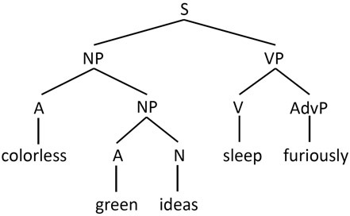

这个结构告诉了我们很多关于语言的东西。首先，它显示了哪些语言单位彼此相属。副词*furiously*（狂怒地）更多地说明了动词*sleep*（睡觉），而不是名词*ideas*（想法）。“想法”是“绿色的”，而“绿色的想法”是“无色的”。这种结构有多方面的证据。说话者在树中高层分支之间停顿的可能性，远大于在较低层分支之间停顿的可能性。所以说话者可能会说“colorless green ideas . . . 嗯 . . . sleep furiously”，这表明这些结构在心理上是直观的。但也许更重要的是，当我们构成不同的句子时，我们移动的是整个单位，而不是单位内部的元素。所以我可能会问“绿色的想法是什么样的？”你可能回答“无色的”。或者问“什么狂怒地睡觉？”你可能回答“无色的绿色想法”。甚至构成疑问句也遵循转换规则。任何说英语的人都知道，如果你想构成“Did the colorless green ideas sleep furiously?”这样的疑问句，你基本上是把原句变成过去时——“colorless green ideas slept furiously”——给句子加上助动词*did*——“colorless green ideas did sleep furiously”——再把助动词移到句首。我们之所以知道这一点，是因为我们心中有语法规则，正如我们心中有转换规则一样。

This structure tells us a lot about language. First, it shows which linguistic units belong to one another. The adverb *furiously* says more about the verb *sleep* than about the noun *ideas*. The “ideas” are “green” and the “green ideas” are “colorless.” The evidence for this structure comes from a variety of pieces of evidence. It is far more likely that a speaker pauses between the branches high up in the tree than branches further down. So a speaker might say “colorless green ideas . . . ehm . . . sleep furiously,” demonstrating these structures are psychologically intuitive. But perhaps even more importantly, we move units around when we form different sentences rather than the elements within the units. So I might ask, “What are the green ideas?” and you may respond “colorless.” Or “what sleeps furiously?” and you may respond, “The colorless green ideas.” Even forming questions follows transformational rules. Any speaker of English knows that if you want to form a question like “Did the colorless green ideas sleep furiously?” you basically put the original sentence in the past tense—“colorless green ideas slept furiously”—add the auxiliary verb *did* to the sentence—“colorless green ideas did sleep furiously”—and move the auxiliary verb to the beginning of the sentence. We know this because we have the grammatical rules in our mind, as we have the transformational rules in our mind.

乔姆斯基关于一种交流的数学理论、一种语言加工软件的提议，需要放在一个更广阔的语境——计算的语境——中来看。1956年在达特茅斯学院举办的一次夏季研讨会上，人工智能领域诞生了，约翰·麦卡锡创造了这个术语。麻省理工学院教授约翰·麦卡锡和马文·明斯基、卡内基梅隆大学教授艾伦·纽厄尔和赫伯特·西蒙，以及IBM研究员亚瑟·塞缪尔参加了这次研讨会。

Chomsky’s proposal of a mathematical theory of communication, a software for language processing, needs to be seen in a broader context, a computational context. At a summer workshop at Dartmouth College in 1956, the field of artificial intelligence was born, when John McCarthy coined the term. MIT professors John McCarthy and Marvin Minsky, Carnegie Mellon professors Allen Newell and Herbert Simon, and IBM researcher Arthur Samuel attended the workshop.

同一年，另一门学科——认知科学——诞生了。<sup>7</sup>1956年9月11日，在麻省理工学院举行了一次信息论专题兴趣小组研讨会。研讨会上有心理学家乔治·米勒关于人类记忆和信息存储的论文，有艾伦·纽厄尔和赫伯·西蒙关于一个复杂信息加工系统的论文，还有乔姆斯基关于形式语法的论文。达特茅斯的研讨会和麻省理工学院的研讨会都洋溢着借助计算机的进步来理解人类心智的热情。人类心智不再是一个只对环境作出反应的黑箱，而是——像计算机一样——拥有独立的思维过程、目标状态和记忆，并且能够执行计划。

That same year, another discipline—cognitive science—was born.<sup>7</sup> A Special Interest Group in Information Theory symposium was held on September 11, 1956, at MIT. The symposium included a paper by psychologist George Miller on human memory and the storage of information, one by Allen Newell and Herb Simon on a complex information-processing system, and one by Chomsky on formal grammars. Both the workshop at Dartmouth and the one at MIT were surrounded with enthusiasm on understanding the human mind in light of the advance of computers. Instead of the human mind being a black box that only functions in response to the environment, the human mind—like a computer—had independent thought processes, goal states, and memory and was able to execute plans.

人们对人类心智和人工心智都充满了热情。通过研究人类心智，我们会更多地了解人工心智；通过构建人工心智，我们会更多地了解人类心智。我常常需要提醒同事和朋友，人工智能已经存在相当长一段时间了，如果没有认知科学的发展，人工智能的许多进展可能根本不会发生。<sup>8</sup>

There was excitement about human minds as well as about the artificial minds. By investigating human minds, we would learn more about artificial minds, and by building artificial minds, we would learn more about human minds. I often need to remind colleagues and friends that artificial intelligence has been around for quite a while, and that many of the developments in AI would probably not have taken place were it not for the developments in cognitive science.<sup>8</sup>

按照诺姆·乔姆斯基和史蒂芬·平克这样的先天论者的说法，语言本能原来就是儿童为何能够如此好地习得语言的答案。还有什么能够解释，为什么世界上任何地方的每一个孩子，无论社会经济地位或认知技能如何，都能毫无问题地习得语言——假设不存在忽视或虐待之类有损儿童正常成长的因素？还有什么能够解释儿童如何能够迅速地习得语言？在满十岁之前，儿童就已经能流利地使用母语了。这一点特别有意思，因为在人生的后期，习得一门新语言似乎要困难得多。

According to nativists like Noam Chomsky and Steven Pinker, language instinct turns out to be the answer as to why children are able to acquire language so well. What else can explain why every child, anywhere in the world, regardless of socioeconomic status or cognitive skills, is able to acquire language without a problem—assuming there are no factors detrimental to normal upbringing of the child, such as neglect or abuse? What else can explain how children are able to acquire language rapidly? Already before they turn 10, children are fluent in their native language. This is particularly interesting, because later on in life, it seems to be so much more difficult to acquire a new language.

所以我们可以说，语言习得得很快，并且似乎有一个依赖年龄的关键期，在此期间语言会被自动习得。它确实是自动的，因为在语言习得上我们没有选择。我可以选择学或不学骑自行车或游泳。但对于语言习得，情况就不同了。我无法逃避习得语言。无论我喜不喜欢，我都具备习得语言的能力。我甚至不需要特别的指导——不像大多数孩子学骑自行车或游泳时那样——也不需要任何特别的鼓励。我父母从来没有许诺习得语言就给我钱，就像他们许诺我带回一份说得过去的成绩单就给我钱那样。（我从来没挣到多少。）这种论证认为，语言不是在强化和惩罚的基础上习得的。世界各地的儿童以相似的速度、在相似的阶段、以大致相同的方式习得语言。

So we could say that language is acquired fast and seems to have an age-dependent critical period during which it is automatically acquired. It is automatic, indeed, as we don’t have a choice in language acquisition. I can choose whether or not to learn how to ride a bike or how to swim. But for language acquisition, it is different. I cannot bail on acquiring language. Whether I like it or not, I am equipped for acquiring language. I do not even need special instructions—as most children do when learning how to ride a bike or how to swim—and do not need any special encouragements. My parents never promised me money for acquiring language, as they did for coming home with an acceptable grade report. (I never made much.) Language is not learned on the basis of reinforcements and punishments, the argument goes. Language is acquired by children all over the world, at a similar speed, in similar phases, in more or less the same way.

鉴于世界各地的儿童，尽管社会经济地位不同，尽管成长和教育经历不同，都以几乎相同的方式学习语言，我们必须假定，世界上所有语言之下都存在某种普遍语法。例如，这样一种普遍语法可能由某种特定结构组成，比如句子的主语位于动词之前。一项考察了世界上5,252种语言词序的大规模研究<sup>9</sup>发现，惊人的83%的语言要么是主语-宾语-动词（SOV）语序，要么是主语-动词-宾语（SVO）语序。SOV语序见于日语、韩语、波斯语和土耳其语等语言；SVO语序见于英语、西班牙语和汉语等语言。另一些语言，比如荷兰语和德语，两头兼顾。它们在从句中使用SOV，在主句中使用SVO。尽管语言可以选择六种不同的语序，但将近4,500种语言偏爱SVO或SOV语序。从来没有设立过什么专门的国际语言学委员会来规定主语、动词和宾语的用法，也从来没有哪个世界语言学委员会规定过SVO或SOV结构。对这种语序的强烈偏好必定表明存在普遍语法的证据。

And given that children all over the world, despite their different socioeconomic status, despite the differences in their upbringing and education, all learn language in pretty much the same way, we must assume that there is some universal grammar underlying all languages in the world. Such a universal grammar may, for instance, consist of a particular structure such as the subject of the sentence preceding the verb. An extensive study<sup>9</sup> that investigated the word order of 5,252 languages in the world found that an astonishing 83 percent either had a subject-object-verb (SOV) order or a subject-verb-object (SVO) order. The SOV order can be found in languages like Japanese, Korean, Persian, and Turkish; the SVO order in languages like English, Spanish, and Chinese. Other languages, like Dutch and German, double-dip. They use SOV in their subordinate clauses and SVO in their main clauses. Despite the fact that languages could choose six different orders, almost 4,500 languages prefer either SVO or SOV word orders. No special International Committee of Linguistics was ever put in place to prescribe the use of subjects, verbs, and objects, and no world committee of linguistics ever prescribed the SVO or SOV structure. The strong preference for that order must suggest evidence for a universal grammar.

但如果论点是语言有一套单一的规则，一种语言中所有合乎语法的句子都可以从中推导出来，那么为什么各种语言看起来彼此如此不同呢？答案是，表面上看起来不同的东西，从其底层来看最终是相同的。一种语言的这种抽象知识——这才是普遍语法中真正重要的东西——可以在句子的深层结构中看到。以句子“Juliet was kissed by Romeo”（朱丽叶被罗密欧亲吻了）为例。尽管这个句子在表面上看起来不同，但在一个更深、更抽象的层面上，它实际上与句子“Romeo kissed Juliet”（罗密欧亲吻了朱丽叶）是相同的。或者以句子“flying planes can be dangerous”为例。这个句子在一个更深、更抽象的层面上可以有不同的意思。如果你没上过任何飞行课，对我们大多数人来说结论很简单：开飞机可能很危险。但至于遥控无人机，对于我们这些站在地面上的人来说，结论是一样的：飞行中的飞机可能很危险。句子的表层结构是一回事；句子的深层结构是另一回事。而在这一理论中，最终起作用的是深层结构。

But if the argument is that language has a single set of rules from which all grammatical sentences in a language can be derived, why do languages look so different from one another? The answer is that what may seem different at the surface is ultimately the same when considering what lies beneath. That abstract knowledge of a language—and that’s really what counts in the universal grammar—can be seen in the deep structure of a sentence. Take for instance the sentence “Juliet was kissed by Romeo.” Even though the sentence looks different on the surface, at a deeper, more abstract level, it really is the same as the sentence “Romeo kissed Juliet.” Or take the sentence “flying planes can be dangerous.” The sentence can mean different things at a deeper, more abstract level. If you have not taken any flying lessons, for most of us the conclusion is simple: flying planes can be dangerous. But as for radiographic drones, the conclusion for those of us standing on the ground is the same: flying planes can be dangerous. The surface structure of a sentence is one thing; the deep structure of a sentence is another. And it is the deep structure that ultimately counts in this theory.

隐藏在句子深层结构中的这种普遍语法，就是把语言映射到语法上的东西。这种普遍语法，也被称为语言习得装置，<sup>10</sup>可以被看作一块心理配电盘，上面有一排需要打开或关闭的开关。学习语言的孩子所需要做的，只是为它所习得的语法打开和关闭开关。例如，想象一个孩子将成为西班牙语使用者。对她来说，打开代词脱落开关很容易，这样你就能生成句子“*Ve este tronco? Sería Bueno para la fogata. Está completamente seco*［看见这根木头了吗？会很适合篝火。完全干了。］”但对于一个学英语的孩子来说，代词脱落开关应当关闭，这样才能生成带代词的句子，比如“Do you see this log? It would be good for the campfire. It is completely dry.”（你看见这根木头了吗？它会很适合篝火。它完全干了。）这些开关，或者乔姆斯基所说的参数，是语言的一个普遍方面。学习语言的孩子在接触语言时设定这些参数，从而限制了孩子试图习得的语法可能的形态。世界各地的语言必定有一种普遍语法，因为世界各地的儿童习得语言的方式是如此相似。

This universal grammar hidden in the deep structure of sentences is what maps language to grammar. That universal grammar, also called language-acquisition device,<sup>10</sup> can be seen as a mental switchboard that has a sequence of switches that need to be turned on or off. All the language-learning child needs to do is to turn on and off switches for the grammar it acquired. For instance, imagine a child becoming a speaker of Spanish. For her it is easy to turn on the pronoun-drop switch so that you can generate the sentence “*Ve este tronco? Sería Bueno para la fogata. Está completamente seco* [See this log? Would be good for the campfire. Is completely dry].” But for a child learning English, the pronoun-drop switch should be turned off, so sentences with a pronoun can be generated, such as “Do you see this log? It would be good for the campfire. It is completely dry.” These switches, or parameters as Chomsky calls them, is a universal aspect of language. The language-learning child sets these parameters as they are exposed to language, thereby constraining the possible shapes of the grammar the child tries to acquire. Languages across the world must have a universal grammar because children across the world acquire language in such similar ways.

史蒂芬·平克认为普遍语法不仅适用于句子，也适用于词。与句子类似，我们心中对词的结构也有直观的规则。以*Trumpianisms*这个词为例。<sup>11</sup>三年前，时任总统特朗普不小心发推说：“Despite the constant negative press covfefe.”（尽管不断有负面的新闻covfefe。）*Covfefe*是*coverage*（报道）的拼写错误，但这个词成了一个网络迷因。*Covfefe*成了一个Trumpianism（特朗普式用语），是若干Trumpianisms之一。即使没有对这个你很可能从未听过的词的解释，你可能也不难理解*Trumpianism*的意思。你会假设*Trumpianisms*很可能是复数，而*Trumpianism*是单数。你大概还能从*Trumpianism*中剥掉-*ism*，得出结论说我指的是某种相当Trumpian（特朗普式）的东西。如果我问某种Trumpian的东西指的是什么，你很可能会回答它指的是特朗普。与句子树结构一样，词的树结构大致如下：

Steven Pinker would take the universal grammar to apply not only to sentences, but also to words. Similar to sentences, we have intuitive rules in our mind for word structure. Take for instance the word *Trumpianisms*.<sup>11</sup> Three years ago, then-President Trump accidentally tweeted, “Despite the constant negative press covfefe.” *Covfefe* was a misspelling of *coverage*, but the word became an internet meme. *Covfefe* became a Trumpianism, one of several Trumpianisms. Without this explanation for a word you likely have never heard before, you would probably have had little difficulty getting to the meaning of *Trumpianism*. You would assume that *Trumpianisms* is likely to be plural, and *Trumpianism* would be singular. You would probably also be able to peel off the -*ism* from *Trumpianism* and conclude I was referring to something rather Trumpian. And if I asked what something Trumpian would be referring to, you would likely respond that it would refer to Trump. As with the sentence tree structure, the word tree structure would look something like this:

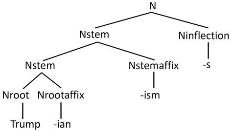

这些规则——无论是适用于句子还是词——对我们来说都是直观的。它们是我们语言本能的一部分。所以，如果人类拥有一种语言习得装置、一种普遍语法、一种语言本能，这可能就是结论。但得出这一结论的论据又是什么呢？

These rules—whether applicable to sentences or words—are intuitive to us. They are part of our language instinct. So if humans have a language-acquisition device, a universal grammar, a language instinct, that may be the conclusion. But what are the arguments arriving at that conclusion?

## 刺激贫乏

## POVERTY OF THE STIMULUS

我们的语言天赋之所以只能来自语言习得装置或语言本能，一个重要的论据是：没有别的来源。人们很容易认为，儿童学习语言只是记住父母说的句子。我们已经知道，父母可以选择的句子库大约有十万亿亿个。一个孩子可能有一种快速学习策略，使她能够模仿父母说过的每一个句子。然而，正在习得语言的孩子能够说出她从未听过的句子。更重要的是，孩子从中学习的语言环境相当贫乏。语言刺激是贫乏的。

An important argument why our knack for language cannot come from anything other than a language-acquisition device or language instinct is that there is nothing else. It would be tempting to think that children learn language by simply memorizing the sentences their parents speak. We already know that the repertoire of sentences parents could choose from is some 10 sextillion. A child could have a fast learning strategy that allows for imitating every sentence that her parent has ever uttered. However, the language-acquiring child is able to speak sentences she has never heard before. And more importantly, the linguistic environment the child learns from is rather poor. There is a poverty of the linguistic stimulus.

想象孩子需要学习什么是正确的合乎语法的句子、什么是不正确的不合语法的句子。她听到口误（“The sky is shining”，天空在照耀）、句子片段（“Good job!”，干得好！）和简化的句子（“Wanna cookie?”，要饼干？）。她听到不完整的句子（“我真正想说的是……啊，算了！”）和不流利的句子（“你能……你能……你能帮帮忙吗？”）。关于不完整和不流利的句子，你可以听听某人打电话，记下说话者使用真正合乎语法的句子有多频繁。并不那么频繁。或者想想大多数人是如何对婴儿说话的：音调高，大量无意义的词，句法结构简化，省略动词和限定词（“Doggie gone!”，狗狗没了！）——有人称之为“妈妈语”（Motherese）。<sup>12</sup>与我们熟悉的句子、以及孩子将来能够说出的句子相比，这些句子更短，发音更清楚，语速更慢，有很多重复，等等。正因为儿童听到的刺激如此贫乏，他们能够开始生成完整的合乎语法的句子、而不是像父母对他们说话那样说妈妈语，这才显得非同寻常。尽管刺激贫乏，儿童仍然能够习得语言，并说出他们从未听过的合乎语法的句子。至少按照某些人的说法，由于刺激质量很差，儿童不可能从刺激本身中学会语法；他们必定拥有一种生成语法，一种语言本能。

Imagine that the child needs to learn what is a correct grammatical sentence and an incorrect ungrammatical sentence. She hears slips of the tongue (“The sky is shining”), sentence fragments (“Good job!”), and simplified sentences (“Wanna cookie?”). She hears incomplete sentences (“What I wanted to say really is . . . ah, never mind!”) and disfluent sentences (“Can you . . . can you . . . can you help?”). For both incomplete and disfluent sentences, listen to somebody on the telephone, and mark how often the speaker uses an actual grammatical sentence. Not that often. Or think about how most people talk to babies: high pitch, lots of nonsense words, simplified syntactic structure with verbs and determiners being skipped (“Doggie gone!”)—what some have called Motherese.<sup>12</sup> Compared to the sentences we are familiar with, and the ones a child will be able to produce, sentences are shorter, articulation is clearer, speech rate is lower, there are many repetitions, and so on. Because the stimulus children hear is so poor, it is remarkable that they are able to start generating full-fletched grammatical sentences and do not start to speak like their parents speak to them, in Motherese. Despite the poverty of the stimulus, children are able to acquire language and produce grammatical sentences that they have never heard before. Because of the poor quality of the stimuli, children cannot learn grammar from the stimuli themselves; they must have a generative grammar, a language instinct, at least according to some.

## 关键期

## CRITICAL PERIOD

人类特有的语言生物能力的进一步证据，来自一个语言被自动习得的关键期。人类在青少年期之前有一个第一语言习得的最佳时期。过了关键期，就不会发展出一个完全复杂的语言系统。存在语言习得关键期的证据来自一项研究，该研究考察了中国和韩国移民习得英语的技能。<sup>13</sup>研究控制了社会经济背景和接触英语的程度。他们抵达美国时的年龄在三岁到三十九岁之间。一项合语法性判断测试表明，三到七岁之间抵达的人，其表现与以英语为母语的人相同。七岁之后，八到十岁之间抵达的人表现降至94%，十一到十五岁之间抵达的人进一步降至87%，十七到三十九岁之间抵达的人降至77%。

Further evidence for a human-specific biological capacity for language comes from a critical period during which language is acquired automatically. Humans have an optimal period for first language acquisition before the teen years. After the critical period, a fully complex language system will not develop. Evidence for a critical period in which language acquisition takes place comes from a study that investigated Chinese and Korean immigrants’ language-acquisition skills of English.<sup>13</sup> The socioeconomic background and exposure to English were controlled for. The ages of arrival in the United States were between three and thirty-nine. A grammaticality judgment test showed that those who arrived between ages three and seven had a performance that was the same as for native speakers of English. After the age of seven, performance dropped to 94 percent for those who arrived between eight and ten, dropped further to 87 percent for those who arrived between eleven and fifteen, and dropped to 77 percent for those who arrived between seventeen and thirty-nine.

移民只有在三到七岁之间学习英语时才能达到母语者的水平，这一事实为关键期提供了证据。但这项研究针对的是学习第二语言的人。我们真正想知道的是，学习母语的儿童是否存在语言习得的关键期。而这样的研究似乎是不可能的，至少是不道德的。剥夺儿童的语言，看看他们——在假定的关键期之后——还能不能学会语言，这是不可能做的。

The fact that the immigrants performed at native-speaker level only if they learned the English language between three and seven years old shows evidence for a critical period. But this study is for those who learned a second language. What we would really like to know is whether there is a critical period for language acquisition in children who learn their native language. And that study seems impossible, or unethical at least. It would not be possible to deprive children of language and see whether—after the presumed critical period—they are able to learn language after all.

令人悲伤的是，确实存在一些——幸好只是极少数——儿童被剥夺了语言的案例。最著名、最令人悲伤的案例是吉妮（Genie）。吉妮生于1957年。从大约二十个月大起，吉妮就被隔离在一个封闭的小房间里，只要她发出任何声音，就会遭到父亲的体罚。她的父亲和哥哥从不和吉妮说话，家里也没有收音机或电视。母亲在喂饭时被禁止和吉妮待超过几分钟。我不再描述吉妮这一非常悲惨的案例的更多细节，只想强调，在可以假定为她能够习得语言的关键期内，她被剥夺了语言。吉妮在十三岁零九个月时获救。被送进医院时，吉妮是一个瘦得令人心痛的孩子，看起来比实际年龄小六七岁。记录吉妮语言发展的苏珊·柯蒂斯给出了一些例子，说明她在寄养家庭得到照顾后后来能够说出的话。<sup>14</sup>

Sadly enough, there are cases—fortunately only very few—where children have been deprived of language. The most notable, sad case is that of Genie. Genie was born in 1957. From about the age of twenty months, Genie had been isolated in a small, closed room and was physically punished by her father if she made any sounds. Neither her father nor her older brother ever spoke to Genie, and there was no radio or television in the house. The mother was forbidden to spend more than a few minutes with Genie during feeding. I will not describe more details of Genie’s very sad case, other than to emphasize that she was deprived of language during what can be presumed as a critical period in which she would be able to acquire language. Genie was rescued when she was thirteen years and nine months old. When admitted to the hospital, Genie was a painfully thin child who appeared to be six or seven years younger than her age. Susan Curtiss, who documented Genie’s language development, gave examples of the speech she was later able to produce after being taken care of in foster homes.<sup>14</sup>

- Applesauce buy store.（苹果酱 买 商店。）  
  Applesauce buy store.
- Man motorcycle have.（男人 摩托车 有。）  
  Man motorcycle have.
- Genie full stomach.（吉妮 饱 肚子。）  
  Genie full stomach.
- Want Curtiss play piano.（要 柯蒂斯 弹 钢琴。）  
  Want Curtiss play piano.
- Father hit Genie cry long time.（父亲 打 吉妮 哭 很久。）  
  Father hit Genie cry long time.
- Mama have baby grow up.（妈妈 有 宝宝 长大。）  
  Mama have baby grow up.

吉妮没有掌握语法。

Genie had not mastered grammar.

另一个在语言剥夺环境中长大的儿童案例是切尔西（Chelsea）。切尔西被诊断为智力迟钝和情绪障碍。实际上，切尔西是听力受损。当她被确诊并配上助听器后，她在三十出头时开始习得语言。经过强化训练，切尔西能够说话了，但她的语言没有句法或形态——例如<sup>15</sup>：

Another case of a child raised in a language-deprived environment is Chelsea. Chelsea was diagnosed as being retarded and emotionally disturbed. In reality, Chelsea was hearing impaired. When she was diagnosed as such and was fitted with hearing aids, she began acquiring language in her early thirties. Intensive training allowed Chelsea to speak, but her language was without syntax or morphology—for example<sup>15</sup>:

- The small a the hat.（这 小 一个 这 帽子。）  
  The small a the hat.
- Richard eat peppers hot.（理查德 吃 辣椒 辣。）  
  Richard eat peppers hot.
- Banana the eat.（香蕉 这 吃。）  
  Banana the eat.
- The boat sits water on.（船 坐 水 上。）  
  The boat sits water on.
- Combing hair the boy.（梳 头发 这 男孩。）  
  Combing hair the boy.
- The woman is bus the going.（女人 是 公交车 这 去。）  
  The woman is bus the going.
- The girl is come the ice cream shopping buying the man.（女孩 是 来 这 冰淇淋 购物 买 这 男人。）  
  The girl is come the ice cream shopping buying the man.
- Daddy are be were to the work.（爸爸 是 是 曾是 到 这 工作。）  
  Daddy are be were to the work.

这些不合语法的句子是语言没有在语言习得关键期内被习得的结果。这种论证认为，在关键期之后习得的母语，不可能像在关键期内习得的母语那样合乎语法。吉妮和切尔西的悲惨案例大概再清楚不过地表明了这一点。

The ungrammatical sentences are the consequence of language not being acquired during the critical period for language acquisition. And native language acquired after the critical period, the argument goes, cannot be as grammatical as native language acquired during the critical period. Presumably the sad cases of Genie and Chelsea showed this all too well.

## 语言大脑

## LINGUISTIC BRAINS

普遍语言本能的证据，理想情况下应来自语言具有遗传基础的证据。例如，我们可以研究一个家族中几代人的语言障碍。如果一种语言障碍在几代人之间保持一致，并且语言本能具有神经学基础，那么我们应该能够通过几代人之间的遗传缺陷找出其遗传基础。这些缺陷被认为与DNA相关，从而为语言提供生物学基础。21世纪初，语言研究界一片兴奋。一个英国家族受困于无法理解复杂句子，在说句子时缺乏句法组织。他们把词放错了顺序。在这些语言障碍中发现了一个特定的基因，<sup>16</sup>即7号染色体上的一段编码，名为FOX2P。语言本能的生物学基础找到了！

Evidence for a universal language instinct would ideally come from evidence for a genetic basis of language. We could, for instance, investigate language disorders in several generations of a family. If a language disorder is consistent across generations and if there is a neurological basis for a language instinct, then we should be able to identify the genetic basis through genetic glitches across the generations. Those glitches are then assumed to be associated with DNA, providing a biological basis for language. In the early 2000s, there was excitement in the language research community. A British family suffered from being unable to understand complex sentences and lacked syntactic organization in producing sentences. They placed words in the wrong order. A specific gene was found in the language disorders,<sup>16</sup> a stretch of code on chromosome 7, named FOX2P. The biological basis for the language instinct was found!

但FOX2P基因只能是答案的一部分。首先，一个家族中的语言障碍可以归因于一个突变基因是一回事，但因此认为这个基因负责正常发育则是另一回事。其次，FOX2P基因还被证明与肺、肠道和心脏有关。<sup>17</sup>但也许最重要的是，FOX2P基因并非人类独有；它也可以在其他物种中找到。而这就带来了一个问题。如果论点是其他任何物种都没有语言本能，而FOX2P基因是语言本能的生物学基础，那么其他物种中就不应该有这个基因。然而，证据确实表明FOX2P基因负责鸟鸣的精细运动控制，也许鸟鸣与人类言语和语言之间存在很强的相似性。<sup>18</sup>

But the FOX2P gene could only be part of the answer. First of all, the fact that a language disorder in a family could be attributed to a mutated gene is one thing, but assuming that this gene is therefore responsible for normal development is another. Secondly, the FOX2P gene also showed to be related to the lungs, gut, and heart.<sup>17</sup> But perhaps most importantly, the FOX2P gene was not reserved for humans; it could also be found in other species. And that posed a problem. If the argument is that the language instinct is not found in any other species, and the FOX2P gene is the biological basis for the language instinct, then the gene is not to be found in other species. However, the evidence did show that the FOX2P gene is responsible for the fine motor control of bird song, and perhaps there is a strong similarity between bird song and human speech and language.<sup>18</sup>

但大脑中难道就没有任何东西能表明存在语言本能吗？嗯，我不确定大脑结构本身是否能证明语言本能的存在，但确实有一些特定区域在语言加工中比其他区域更活跃。认为语言加工时并非整个大脑都在活动是错误的（就像认为我们只用了大脑的一小部分一样错误，你有时会在聚会上听到这种说法）。每当我们听言语或阅读时，大脑的许多部分都是活跃的：你的运动皮层和感觉皮层（横跨你耳朵上方的那条“发箍”），你的视觉皮层（头的最后部），但在语言加工中最活跃的是覆盖你前额和耳朵的那些区域，特别是左侧。对于大约90%的右利手者，语言加工发生在左半球；对于大约50%的左利手者，语言在两个半球甚至在右半球加工。再深入看看语言区，有两个区域格外突出。一个叫布洛卡区，另一个叫韦尼克区。

But is there nothing in the brain that would suggest a language instinct? Well, I am not sure whether brain structures would demonstrate a language instinct per se, but it is the case that specific areas are more active in language processing than other areas. It would be a mistake to not think the entire brain is active in language processing (the same mistake as to think that we only use a small portion of our brain, as you sometimes hear at parties). Whenever we listen to speech or read, many parts of our brain are active: your motor and sensory cortex (the “hairband” over your ears), your visual cortex (the very back of your head), but most active in language processing are the areas that cover your forehead and your ear, the left side specifically. For about 90 percent of right handers, language processing takes place in the left hemisphere, and for about 50 percent of left-handers, it is processed in both hemispheres or even in the right hemisphere. And digging a little deeper in language areas, two areas stand out. One is called Broca’s area, the other Wernicke’s area.

布洛卡区以十九世纪法国医生、解剖学家和人类学家皮埃尔·保罗·布洛卡的名字命名。1861年，布洛卡描述了一位中风患者。这位患者随后出现了说话困难。发音、吹口哨和唱歌仍然相对正常，但说出句子却变得极其困难。不过他的语言理解技能仍然完好。他能够理解言语。患者去世后，布洛卡发现大脑的一个特定部位有损伤。后来，大约八位有类似语言障碍的患者在大脑的同一区域也有损伤，这个区域如今被称为布洛卡区，位于大脑左侧太阳穴附近。下面你看到的是患者M.E.的一个例子（使用首字母缩写以保护患者隐私）。<sup>19</sup>

Broca’s area is named after nineteenth-century French physician, anato-mist, and anthropologist Pierre Paul Broca. In 1861, Broca described a patient who had a stroke. The patient then had difficulties speaking. Pronouncing words, whistling, and singing were still relatively normal, but speaking sentences turned out to be extremely difficult. But his language-comprehension skills were still intact. He was able to understand speech. After the patient had passed away, Broca found that a specific part of the brain had damage. Later, some eight patients with similar language impairments had damage in the same area of the brain, an area that is now called Broca’s area, around the left temple of the brain. Below you see an example of patient M.E. (initials are used to protect the privacy of the patient).<sup>19</sup>

> 啊……星期一……啊爸爸和保罗和爸爸……医院。两个……啊，医生……和啊……三十分钟……和是的……啊……医院。和，呃，星期三……九点。和呃星期四，十点……医生。两个医生……和啊……牙齿。

> Ah . . . Monday . . . ah Dad and Paul and Dad . . . hospital. Two . . . ah, doctors . . . and ah . . . thirty minutes . . . and yes . . . ah . . . hospital. And, er, Wednesday . . . nine o’clock. And er Thursday, ten o’clock . . . doctors. Two doctors . . . and ah . . . teeth.

我们仍然能听懂这位患者的话，但问题似乎出在句子的合语法性上。句子结构受损了。

The speech of the patient we can still follow, but the grammaticality of the sentences seems to be the problem. The sentence structure is impaired.

韦尼克区是大脑中另一个在语言加工中起核心作用的区域。你可能已经猜到了，韦尼克区也是以首先把该区域与语言障碍联系起来的科学家的名字命名的，他就是十九世纪德国神经学家和精神病学家卡尔·韦尼克。他的一组中风患者与布洛卡失语症患者不同，在语言产出上没有问题，但在理解书面语和口语上却有困难。一个著名的韦尼克失语症患者言语的例子是C.B.，他被给看了一幅图，图上两个孩子趁母亲背过身去时从饼干罐里偷饼干：

Wernicke’s area is another area in the brain that plays a central role in language processing. As you may have guessed, Wernicke’s area is also named after the scientist who first linked the area to the language impairment, nineteenth-century German neurologist and psychiatrist Carl Wernicke. A group of his patients who had a stroke had no problems with the production of language, as with Broca’s aphasia patients, but did struggle with the comprehension of written and spoken language. A well-known example of speech by a Wernicke’s aphasia patient is that of C.B., who was shown a picture of two children stealing cookies out of a cookie jar while their mother’s back was turned:

> 嗯这是……母亲不在这里工作她的工作从这里出去让她变得更好，但是当她在看的时候，两个男孩在看另一部分。一个他们的小瓷砖进入她的时间这里。她在一起工作而一个在这里偷偷摸摸地转来转去，做他的工作和他进一步的好玩他拥有的他的时间。<sup>20</sup>

> Well this is . . . mother is away here working her work out o’ here to get her better, but when she’s looking, the two boys looking in the other part. One their small tile into her time here. She’s working together and one is sneakin’ around here, making his work an’ his further funnas his time he had.<sup>20</sup>

布洛卡失语症和韦尼克失语症的案例表明，大脑显然有专门负责特定功能的区域，语言加工就是其中之一。更具体地说，韦尼克区的核心是由颞平面构成的。据报道，左半球的颞平面比右半球的大五倍。<sup>21</sup>也许颞平面就是我们一直在寻找的语言器官？在一项研究中，研究者比较了三个月大的婴儿在清醒和睡眠时听到正常言语和倒放言语时的大脑活动。在成人身上活跃的语言区，包括颞平面，在婴儿身上同样活跃，尽管他们还不会说话，大概也不理解语言。<sup>22</sup>

What the cases of Broca’s and Wernicke’s aphasia show is that apparently the brain has areas dedicated for particular functions, language processing being one of them. More specifically, the heart of Wernicke’s area is formed by the planum temporale. The planum temporale is reported to be five times larger in the left hemisphere than in the right hemisphere.<sup>21</sup> Perhaps the planum temporale is the language organ we have been looking for? In one study, brain activity was compared in three-month-old infants when presented with normal speech and reversed speech when they were awake and when they were asleep. The language areas that are active in adults, including the planum temporale, were also active in infants, despite the fact that they were not able to speak or presumably understand language.<sup>22</sup>

在另一项脑成像研究中，以德语为母语的人被呈现了意大利语和日语样本，以及一种违反普遍语法规则的人造语言。脑成像实验的结果表明，布洛卡区参与了对普遍语法句法规则（意大利语和日语）的习得，但没有参与对人造语法的习得。那么，也许布洛卡区就是语言本能在神经学上缺失的那一块？<sup>23</sup>

In another brain-imaging study, German native speakers were presented with Italian and Japanese samples and with an artificial language that violated the rules of a universal grammar. The results of the brain-imaging experiment showed that Broca’s area was involved in the acquisition of syntactic rules of the universal grammar (Italian and Japanese) but not for the artificial grammar. Perhaps Broca’s area, then, is the neurologically missing piece of the language instinct?<sup>23</sup>

## 普遍语法

## UNIVERSAL GRAMMAR

人类拥有一种普遍语言、一种语言习得装置、一种语言本能的观点主导语言学已有几十年。但如果普遍语法如此普遍，找出这种语法的要素应该很容易。我们可以说，提出一种统一的普遍语法并不那么容易，因为不同语言之间可能存在细微差别，但按照乔姆斯基的说法，普遍语法的原则其实是没有例外的。<sup>24</sup>尽管有数以百计的科学论文讨论普遍语法，但即使在这个概念提出七十年之后，也仍然不存在一本普遍语法手册。如果它构成了我们人类独有的语言本能的支柱，这就相当令人惊讶了。幸运的是，一些语言学家已经就普遍语法会是什么样子提出了建议。但当比较其中十<sup>25</sup>个建议时，没有两个是相同的。它们几乎在每个方面都各不相同！

The idea of humans having a universal language, a language-acquisition device, a language instinct has dominated linguistics for decades. But if the universal grammar is so universal, it should be easy to identify the elements of that grammar. We may argue that coming up with a unified universal grammar is not that easy because there may be small differences across languages, but according to Chomsky, the principles of universal grammar are really exceptionless.<sup>24</sup> Despite hundreds of scientific articles that discuss a universal grammar, a handbook of universal grammar does not exist, not even seventy years after the concept was introduced. And that is rather surprising if it forms the backbone of our uniquely human language instinct. Luckily some linguists have made proposals on what a universal grammar would look like. But when ten<sup>25</sup> of these proposals are compared, none of them are the same. They vary in almost every aspect!

但也许我们真正应该看的不是普遍语法的要素，而是一般原则，比如语言中主语-动词-宾语的排序。我们不是已经得出结论说，将近4,500种语言的深层结构是SVO或SOV语序吗？这肯定构成了某种普遍性。的确，值得注意的是，所有语言中有83%使用六种语序选项中的两种。但当考虑语言*语系*时，这个数字降到了70%。此外，六种语序组合中的每一种都能找到语言实例。

But perhaps we should really look not at the elements of universal grammar but at the general principles, such as the ordering of subject-verb-object in languages. Did we not conclude that almost 4,500 languages either had SVO or SOV order in their deep structure? That would surely constitute some universality. Indeed, it is noteworthy that 83 percent of all languages use two out of the six word-order options. But when language *families* are considered, the number drops to 70 percent. Moreover, examples of languages for all six word-order combinations can be found.

支持普遍语法的最核心论据之一是刺激贫乏。儿童从未接触过他们能够生成的那些合乎语法的句子。但可以论证的是，刺激并不贫乏，而是丰富的。考察儿童导向言语实际质量的研究发现了与刺激贫乏论据截然相反的情况。在对儿童说的1,500个句子中，只有一个句子——没错，不到0.1%——是不合语法的。尽管有人认为，父母比我们在由更多陈述句组成的对话中提出更多问题、使用更多祈使句这一事实是支持刺激贫乏论据的证据，<sup>26</sup>但另一些人认为，父母采取的“少即是多”的方式——从较简单的话语开始，慢慢地但确定无疑地建立起更复杂的话语——实际上有助于儿童习得语言！<sup>27</sup>

One of the most central arguments for a universal grammar was the poverty of the stimulus. Children are never exposed to the grammatical sentences they are able to generate. But the argument can be made that there is not a poverty of the stimulus but a richness of it. Studies that looked at the actual quality of child-directed speech found something in stark contrast to a poverty of the stimulus argument. Out of the 1,500 sentences spoken to children, only one sentence—that’s right, less than 0.1 percent—was ungrammatical. And even though some have argued that the fact that parents ask more questions and use more imperatives than in conversations we have, which consist of more declarative sentences, is evidence in favor of a poverty-of-the-stimulus argument,<sup>26</sup> others have argued that the less-is-more approach that parents take, starting with simpler utterances and slowly but surely building on to more complex utterances, in fact helps children to acquire language!<sup>27</sup>

对于“儿童以惊人的速度习得语言”这一论点，我们也可以在页边写上一些评语。如果儿童能在三个月到五岁之间学会语言，人们可以反驳说，他们实际上起步更早，因为研究表明，儿童在子宫里就已经在获取语言信息了。<sup>28</sup>也许不太是复杂的句法信息或语义信息，但肯定有关于言语语调的信息，而这些信息反过来至少可能会影响语法。此外，什么是*快*？五年零三个月（如果把胎儿在子宫里获取的信息也算上，就是六年）可能算快，但一切都是相对的。大多数婴儿在九到十二个月之间迈出第一步，到十四或十五个月大时就能到处走了。所以在六个月之内，他们就能走路了。<sup>29</sup>或者，在六到十八个月大时开始学游泳的婴儿，大约需要一到两年才能学会在水中保证安全。我并不是在拿走路或游泳与语言习得作比较，但把六年放在婴儿习得其他技能的语境中来看，就可以提出什么是*快*的问题。

We may also place comments in the margin on the argument that children acquire language at an amazing speed. If children are able to learn language between three months and five years, one can object that they actually had an earlier head start, as studies have shown that children already acquire linguistic information while being in the womb.<sup>28</sup> Perhaps not so much complex syntactic information or semantic information, but certainly information about intonation of speech that may in turn affect at least grammar. Besides, what is *fast*? Five years and three months (or six years if you count the information the fetus acquires in the womb) may be fast, but everything is relative. Most babies take their first steps sometime between nine and twelve months and are able to walk around by the time they are fourteen or fifteen months old. So within six months, they are able to walk.<sup>29</sup> Or babies who begin to learn to swim between six and eighteen months old will take around one to two years to learn to be safe in the water. I am not comparing walking or swimming with language acquisition, but place six years in the context of other skills being acquired by babies, and the question can be raised what *fast* is.

但至少吉妮和切尔西的案例证明了存在语言习得关键期，不是吗？嗯，其实不然。加州大学洛杉矶分校教授维多利亚·弗罗姆金带领一个语言学家团队对吉妮的语言发展进行了研究。她的一名研究生苏珊·柯蒂斯负责对吉妮进行测试和记录。吉妮的案例被用作支持关键期的证据，但研究者们自己写了一篇题为《吉妮的语言发展：一个超出“关键期”的语言习得案例》（“The Development of Language in Genie: A Case of Language Acquisition Beyond the ‘Critical Period’”）的论文，其摘要写道：

But at least the cases of Genie and Chelsea demonstrate a critical period for language acquisition, don’t they? Well, not really. UCLA professor Victoria Fromkin led a team of linguists who conducted the research on the language development of Genie. One of her graduate students, Susan Curtiss, did the testing and recording of Genie. Genie’s case has been used as evidence in favor of a critical period, but the researchers themselves wrote a paper titled “The Development of Language in Genie: A Case of Language Acquisition Beyond the ‘Critical Period,’” the abstract of which reads:

> 本文报告了一个现年16岁的女孩的案例，她一生中的大部分时间都遭受着极端程度的社会隔离和经验剥夺。本文总结了她在假设的“关键期”之后所发生的语言习得，以及这一语言发展与大脑半球成熟和偏侧化发展相关的意义。<sup>30</sup>

> The present paper reports on a case of a now-16-year-old girl who for most of her life suffered an extreme degree of social isolation and experiential deprivation. It summarizes her language acquisition which is occurring past the hypothesized “critical period” and the implications of this lan guage development as related to hemispheric maturation and the development of lateralization.<sup>30</sup>

但让我们假设最初记录吉妮案例的研究者完全弄错了。还有切尔西的案例。切尔西在涉及语法的任务上表现很差，但在涉及词汇的任务上表现良好。但同样，报告切尔西案例的研究者苏珊·柯蒂斯并没有主张关键期，而是指出了一些不同的东西。她说：“在儿童及其语言学习机制正常、但语言学习环境不正常的情况下……人们会发现相对完好的语法习得，伴随着问题较多的语用发展……而且有些研究者认为，词汇发展也有问题。”<sup>31</sup>

But let’s assume that the original researchers documenting Genie’s case had it all wrong. There is the case of Chelsea. Chelsea performed poorly on tasks in which grammar was involved but did well on tasks in which vocabulary was involved. But again, the researcher reporting the Chelsea case, Susan Curtiss, does not argue for a critical period, but points out something different. She states, “In cases where the child and her language learning mechanisms are normal, but the language learning circumstances are not . . . one finds relatively intact grammar acquisition alongside more problematic pragmatic development . . . and, some researchers argue, lexical development as well.”<sup>31</sup>

吉妮和切尔西都被严重剥夺了一切环境刺激。在这两个案例中，都报告了认知缺陷，而把吉妮和切尔西在习得语法方面的问题孤立出来、与她们必须克服的所有其他问题分开来看，至少是有问题的。

Both Genie and Chelsea were severely deprived of environmental stimuli altogether. In both cases, deficient cognition was reported, and it is at least problematic to attribute problems Genie and Chelsea had in acquiring grammar in isolation, separate from all the other problems they had to conquer.

还有一个支持语言本能的论据：人类有语言，而其他物种没有。就我们所知，这是对的。我们可以把语言学习实验视为证据，表明其他物种无论训练者付出多大努力，都无法学会类似人类的语言。这是语言之杯半空的看法。但“动物学不会类似人类的语言——因此人类拥有语言本能”这一结论下得太快了。我们也可以认为，尽管有种种差异，动物能够首先为词语和语法结构赋予一些基本意义，这本身就是个奇迹。按照平克的论证：“我们首先应该为……［动物的］语法研究竟然是可能的而感到惊叹！”<sup>32</sup>

Then there is the argument in favor of a language instinct because humans have language, and other species do not. That is true, as far as we know. We can consider the language-learning experiments as evidence that other species, regardless of all the efforts trainers put in, are unable to learn human-like language. That is the linguistic glass being half empty. But the conclusion that animals do not learn humanlike language—and therefore humans have a language instinct—is a conclusion that is drawn too quickly. We could also argue that despite all the differences, it is miraculous that animals are able to acquire some basic meaning to words and grammatical structures in the first place. To follow Pinker’s argument, “We should be impressed, first and foremost, that research on . . . grammar [in animals] is even possible!”<sup>32</sup>

而且，为什么动物没有习得人类语言这一事实就是语言本能的证据呢？也许它应该是支持这些动物所处环境作用的论据。毕竟，生活在野外的动物与圈养动物之间显然存在差异。环境显然很重要。

And why would the fact that animals do not acquire human language be evidence for a language instinct? Perhaps it should be an argument for the role of the environment these animals live in. After all, there are clearly differences between animals living in the wild and animals living in captivity. Environment apparently matters.

一项仔细分析了五只黑猩猩（其中包括瓦肖）的3,448个手语话语的综述研究得出结论：黑猩猩主要用手势表示物体和动作；它们在手势组合中并没有表现出语义或句法结构的证据。如果有较长的手势组合，也只是表现出重复。简而言之，手势的使用与儿童语言都有差异，更不用说成人的人类语言了。

An overview study that carefully analyzed 3,448 sign utterances from five chimpanzees (among them Washoe) came to the conclusion that chimps primarily use signs for objects and actions; they do not demonstrate evidence for semantic or syntactic structure in combinations of signs. If there were longer combinations of signs, they showed repetition. In short, sign use showed differences with child language, let alone adult human language.

让我们回到教黑猩猩“尼姆·奇姆斯基”语言的赫伯特·S. 特勒斯。尽管特勒斯最初的假设是动物学习言语行为的方式与人类相同，即通过条件作用，正如我们在上一章中看到的那样，但他的结果最终证实了乔姆斯基的观点，即语言是人类独有的。<sup>33</sup>尼姆的语法不是人类的语法。但最近，特勒斯得出了一个有些不同的结论。在《为什么黑猩猩学不会语言而只有人类能学会》（*Why Chimpanzees Can’t Learn Language and Only Humans Can*）<sup>34</sup>一书中，特勒斯并没有主张语言本能——尽管他的结果可能会让其他人认为应该这样主张。相反，他认为尼姆之所以学不会语言，是因为他造不出句子，而他造不出句子，是因为尼姆甚至连词都学不会。把尼姆的语言技能与人类的语言技能区分开来的，不只是语法的缺失。尼姆不能使用词语，也不能给物体命名。特勒斯认为，词语和语法一样，都是语言的基石。

Let’s go back to Herbert S. Terrace, who taught the chimpanzee “Nim Chimpsky” language. Even though Terrace’s original hypothesis was that animals learned verbal behavior the way humans learned verbal behavior, through conditioning, as we have seen in the previous chapter, his results ultimately confirmed Chomsky’s view that language is uniquely human.<sup>33</sup> Nim’s grammar was not human grammar. But recently, Terrace reached a somewhat different conclusion. In *Why Chimpanzees Can’t Learn Language and Only Humans Can*,<sup>34</sup> Terrace didn’t argue for a language instinct—even though his results may have suggested to others that this should be argued. Instead he argued that Nim couldn’t learn language because he couldn’t create sentences because Nim couldn’t even learn words. It was not just the absence of grammar that distinguished Nim’s language skills from those of humans’. Nim was not able to use words and name objects. Terrace argues that words, as much as grammar, are the cornerstones of language.

先天论者支持普遍语法的最后一个论据是那个假设的语言习得装置，即语言本能在大脑中的位置。所有神经科学证据都表明，我们的语言器官必定位于左半球。<sup>35</sup>但左侧优势在鸟类甚至蛙类中也存在，而我们刚刚得出结论说其他物种没有语言。<sup>36</sup>

A final argument made by nativists for a universal grammar was the hypothetical language-acquisition device, the location of the language instinct in the brain. All the neuroscience evidence suggests that our language organ must be housed in the left hemisphere.<sup>35</sup> But there is a dominance for the left side also in birds and even in frogs, and we had just concluded that other species do not have language.<sup>36</sup>

如果我们深入左半球，我们可能会得出结论，至少人类是在布洛卡区和韦尼克区加工语言的。那么那里必定就是语言器官的所在。如果考虑韦尼克区，也许颞平面就是该看的地方。但韦尼克区在大猩猩等类人猿中也能找到。<sup>37</sup>

If we look deeper in the left hemisphere, we might conclude that at least humans process language in Broca’s and Wernicke’s areas. That must then be the location of the language organ. If we consider Wernicke’s area, perhaps the plenum temporale is the place to look. But Wernicke’s area can also be found in great apes.<sup>37</sup>

FOX2P基因可能仍然令人兴奋。语言的遗传基础可能就在于这个基因。嗯，结果发现，FOX2P基因似乎与无法协调运动动作以发出声音有关。这个基因在老鼠身上也能找到，而老鼠是一种缺乏语言本能的动物（名叫米奇的那只除外）。<sup>38</sup>

The FOX2P gene might still be reason for excitement. The genetic basis for language might lie in this gene. Well, it turns out that the FOX2P gene seems to be related to the inability of coordinating motoric movements to form sounds. The gene can also be found in mice, an animal lacking the language instinct (the one named Mickey being excluded).<sup>38</sup>

关于语言本能已经有过大量讨论。无论儿童的环境在语言上是丰富还是贫乏，无论刺激贫乏的论据是难以还是易于成立，很少有人会否认儿童能够从他们接触到的语言中提取句法。无论儿童习得语言相对较快还是相对较慢，无论关键期的论据是难以还是易于成立，儿童能够习得语言的方式都简直令人惊叹。鹦鹉或黑猩猩能否被教会语言技能，是一场关于语言之杯半空还是半满的持续讨论。无论如何，这方面的研究让我们对动物认知有了很多了解，至少让我们在炫耀自己优越的认知技能时谦虚了一些。而无论我们是否有一个语言器官，一个专门为语言加工而配备的大脑模块，没有人会否认，要习得语言，必须有大脑——人类的大脑。

There has been a lot of discussion on the language instinct. Whether or not the environment of the child is linguistically rich or poor, whether the argument for a poverty of the stimulus may be difficult or easy to make, there are few who would deny that children are able to extract syntax out of the language exposed to them. And whether children are relatively quick or relatively slow in acquiring language, whether the argument for a critical period may be difficult or easy to make, the way children are able to acquire language simply is remarkable. Whether parrots or chimpanzees are able to be taught language skills is an ongoing discussion of the linguistic glass being half empty or half full. In any case, this line of research has taught us a lot about animal cognition, and has at least humbled us in our bragging about our superior cognitive skills. And whether we have a language organ, a module in the brain specifically equipped for language processing or not, nobody would deny that one needs to have the brains—the human brains—to acquire language.

然而，我一直无法理解的是那种认为意义不重要、句法才是魔法的论点。对我来说，句法和语义是内在地交织在一起的。词的意义决定了句法结构的构成方式。读句子“The culprit killed the victim”（凶手杀了受害者）比读“The victim killed the culprit”（受害者杀了凶手）更难，尽管这两个句子在句法上同样可以接受。而且正如我在第3章中所论证的，如果句法把读者引上了花园路径，那么通过提供有意义的语境，句法上的困惑就可以很容易地得到纠正。

Yet what I have never been able to get my head around is the argument that meaning does not matter, that it is syntax that is the magic. To me syntax and semantics are intrinsically intertwined. The meaning of words determines the way syntactic constructions are formed. It is harder to read the sentence “The culprit killed the victim” than “The victim killed the culprit,” even though both sentences are equally acceptable in terms of their syntax. And as I argued in chapter 3, if syntax is leading readers astray along a garden path, the syntactic confusion can be quite readily remedied by providing meaningful context.

但也许最重要的是，我一直不太能理解先天论者从语言规律推出语言本能的逻辑。我觉得语言存在数学结构是很耐人寻味的——尽管跨语言来看这些结构有许多例外。但如果语言有一种数学，为什么需要一个语言器官？如果语言中存在规律，为什么这些规律需要由心理参数来支配？为什么人类有语言而其他物种没有这个问题的答案，不能在别处、在语言习得装置之外、在语言本能之外、在语言本身之中找到呢？并不是说主张语言本能是错误的；它只是似乎不完整，也许就像主张语言只能通过训练来习得一样不完整。

But perhaps most importantly, I have never quite been able to understand nativists in the logic that language regularities bring us to a language instinct. I find it intriguing to see there are mathematical structures to language—despite the many exceptions to these structures across languages. But if there is a mathematics to language, why does there need to be a language organ? If there are regularities in language, why would that need to be governed by mental parameters? Why might the answer to why humans have language while other species do not be found somewhere else, outside of the language-acquisition device, outside of the language instinct, in language itself? It is not that arguing in favor of a language instinct is wrong; it just seems incomplete, perhaps as incomplete as arguing that language can only be acquired through training.

• *6* •

• *6* •

# 网络

# Network

> 这些模型假定，信息加工是通过大量被称为单元的简单加工元素之间的相互作用而进行的，每个单元都向其他单元发送兴奋性和抑制性信号。在某些情况下，这些单元代表关于某些事物的可能假设，比如某个特定显示中的字母，或某个特定句子中词语的句法角色。……因此，例如关于一个词是什么的假设，本身就分布在大量单元的激活之中。

> These models assume that information processing takes place through the interactions of a large number of simple processing elements called units, each sending excitatory and inhibitory signals to other units. In some cases, the units stand for possible hypotheses about such things as the letters in a particular display or the syntactic roles of the words in a particular sentence. . . . Thus a hypothesis about the identity of a word, for example, is itself distributed in the activations of a large number of units.

> ——詹姆斯·麦克莱兰、戴维·鲁梅尔哈特和杰弗里·辛顿<sup>1</sup>

> —James McClelland, David Rumelhart, and Geoffrey Hinton<sup>1</sup>

*让*我们来聊聊金丝雀。关于它们你知道些什么？如果你问我这个问题，我会回答：金丝雀是鸟。它们有翅膀，会飞。它们常常是黄色的。它们有喙。它们吃鸟食。而且因为金丝雀是鸟，我知道它们是动物，因此它们是有生命的。它们常常被养在鸟笼里当宠物。我认识的一只金丝雀叫翠迪（Tweety），她被一只叫西尔维斯特（Sylvester）的猫追赶。大概就是这样的回答。

*L*et’s talk canaries. What do you know about them? If you asked me this question, I would answer that canaries are birds. That they have wings and fly. They are often yellow. They have a beak. They eat bird seed. And because canaries are birds, I know they are animals, and therefore they are animate. They are often held in a bird cage as a pet. And one instance of a canary I know is called Tweety, and she is chased by a cat, Sylvester. An answer like that.

我开始这一章的目的，并不是要详细介绍*serinus canaria forma domestica*，也就是家养金丝雀，而是要提出一个不同的问题。这个问题不是关于我们对金丝雀知道些什么，而是关于我们*如何*知道我们对它们所知道的东西。我们心中对金丝雀的表征是什么性质的？这个问题是认知科学的核心问题，也是计算机科学和人工智能的核心问题。毕竟，如果我们知道一个词的意义是如何嵌入一个意义网络之中的，我们也许就能构建出能够回答问题的计算机程序。而这些计算机程序的人工心智可能以与我们人类心智相似的方式运作，从而帮助我们回答我们如何把那些词记在心里这个问题。

It is not my objective to start this chapter giving an exposé of the serinus canaria forma domestica, also called the domestic canary, but to ask a different question. A question not about what we know about canaries, but about *how* we know what we know about them. What is the nature of the representation of canaries we have in our mind? This question is most central to the cognitive sciences, as well as to computer science and artificial intelligence. After all, if we know how the meaning of a word is embedded in a network of meanings, we might be able to build computer programs that can answer questions. And the artificial minds of these computer programs might operate in a similar way as our human minds, and thus help us in the answer to our question of how we keep those words in mind.

试图回答“我们心中对金丝雀（以及任何其他概念）的表征是什么性质的”这一问题的研究者提出，我们是通过语义网络——词义的网络——来理解*canary*（金丝雀）这个词的意义的。这种网络的一种实例是层级网络，它通过在概念之间设置语义关系，把概念彼此联系起来。<sup>2</sup>例如，我们知道金丝雀是鸟，鸵鸟和企鹅也是，而鸟是动物。与此同时，鸟与哺乳动物相区别，哺乳动物的三个实例是人、猫和鲸。

Researchers trying to answer the question of what the nature of the representation of canaries (and any other concept) we have in our mind is have proposed that we understand the meaning of the word *canary* through semantic networks, networks of meanings of words. One instantiation of such a network is a hierarchical network that places concepts in relation to one another by placing semantic relations between them.<sup>2</sup> For instance, we know that canaries are birds, as are ostriches and penguins, and that birds are animals. Meanwhile, birds distinguish themselves from mammals, three instances of which are humans, cats, and whales.

[figure not shown]

这种表征的好处是，我们只需要知道较高层级类别的属性，就能自动知道较低层级类别的属性。动物会吃东西、会呼吸；因此鸟会吃东西、会呼吸，翠迪也是如此。语义网络在认知经济性方面非常出色：我不需要知道一个词的所有特征。我需要知道的只是这个词所属的那个概念词（它的上义词）的特征，这样翠迪就从*canary*那里继承特征，*canary*从*bird*（鸟）那里继承特征，*bird*又从*animal*（动物）那里继承特征。

The advantage of this representation is that we only need to know the properties of the higher-level categories to automatically know the properties for the lower-level categories. Animals eat and breathe; birds thus eat and breathe, and so does Tweety. The semantic network excels in cognitive economy: I don’t need to know all the features for a word. All I need to know are the features of the concept word the word in question falls under (its hypernym), so that Tweety inherits the features from *canary*, *canary* inherits the features from *bird*, and *bird* the features from *animal*.

这种层级语义网络似乎是思考我们概念世界的一种简便方式：一个关于我们心中所有概念的层级模型，与我们心中所有的词相关联。而且层级语义网络不仅在理论上有意思，也得到了经验支持。当向参与者呈现“金丝雀会唱歌”（网络中低层的属性与网络中低层的概念相连）、“金丝雀有羽毛”（网络中中层的属性与网络中低层的概念相连）和“金丝雀有皮肤”（网络中高层的属性与网络中低层的概念相连）这样的句子时，他们判断句子真假所需的时间随网络层级的增加而增加。“金丝雀会唱歌”这个句子几乎不需要时间就能核实，“金丝雀有皮肤”核实所需的时间最长，而“金丝雀有羽毛”正好介于两者之间。正如若干实验所表明的，词语在记忆中似乎是层级组织的。<sup>3</sup>

This hierarchical semantic network seems to be an easy way to think about our conceptual world: a hierarchical model of all the concepts we have in our minds, related to all the words in our mind. And the hierarchical semantic network is not only theoretically interesting but also empirically supported. When participants are presented with sentences like “Canaries can sing” (a property low in the network linked to the concept low in the network), “Canaries have feathers” (a property medium-high in the network linked to the concept low in the network), and “Canaries have skin” (a property high in the network linked to the concept low in the network), the time it takes them to decide whether the sentence is true or not is higher with the increasing levels in the network. The sentence “Canaries can sing” takes hardly any time to verify, “Canaries have skin” takes the longest to verify, and “Canaries have feathers” falls right in between. Words seem to be organized hierarchically in memory, as shown in several experiments.<sup>3</sup>

但尽管它很有魅力，层级模型也面临一些挑战。例如，我们把鸵鸟和企鹅放在哪里？我们可以把它们放在鸟的层级上，但鸵鸟真的与金丝雀和知更鸟处于同一层级吗？还是应该再细分层级？我不知道你怎么看，但对我来说，金丝雀更像知更鸟，而不像鸵鸟或企鹅。那鸭嘴兽我们又该怎么办呢？鸭嘴兽有喙、会下蛋，因此肯定属于鸟（属于鸟类中的鸵鸟阵营，因为鸭嘴兽不会飞）。但鸭嘴兽会游泳，因此属于鱼。但鸭嘴兽在生物学上是哺乳动物，尽管哺乳动物不下蛋而鸭嘴兽下蛋。也许鸭嘴兽是鸟、鱼和哺乳动物的一个例外，但这个例外确实把层级网络搞乱了。

But despite its charm, there are some challenges with the hierarchical model. For instance, where do we place ostriches and penguins? We could place them at the level of birds, but are ostriches really at the same level as canaries and robins? Or should there be a subdivision of levels? I don’t know about you, but to me canaries are more like robins than like ostriches or penguins. And what do we do with the platypuses? A platypus has a beak and lays eggs, and thus definitely belongs to birds (the ostrich camp of the birds, as platypuses do not fly). But a platypus swims and thus belongs to fish. But a platypus biologically is a mammal, though mammals don’t lay eggs and platypuses do. Perhaps the platypus is an exception to the birds, fish, and mammals, but an exception that does mess up the hierarchical network.

我想每条规则你都总能找到例外，也许鸵鸟、企鹅和鸭嘴兽就是鸟类规则的例外（在此向鸵鸟、企鹅和鸭嘴兽诚挚道歉，把它们单独挑了出来！）。但层级语义网络还带来更多问题。对于那些难以用层级网络来考虑的概念，我们该如何处理？我们把鹅卵石放在哪里？猫砂呢？街道呢？灰尘呢？有那么多概念很难放进一个被另一个类别统辖的类别中。层级网络很难说是词语如何被放进语义网络的全部故事。

I guess you can always find exceptions to every rule, and perhaps ostriches, penguins, and platypuses are the exceptions to the bird rule (with sincere apologies to the ostriches, penguins, and platypuses for singling them out!). But the hierarchical semantic network poses more problems. How do we deal with concepts that are difficult to consider in terms of a hierarchical network? Where do we place a cobblestone? Cat litter? Street? Dust? There are so many concepts that are difficult to put in a category overlooked by another category. A hierarchical network can hardly be the entire story how words are placed in a semantic network.

若干研究者恰恰意识到了这一点，并考虑用层级网络之外的另一种表征来说明我们如何把那些词记在心里。与其考虑一个概念继承另一个概念特征的层级，也许我们应该从原型的角度来思考语义网络。这样，我们心中就有一些原型概念，我们把不同的概念与原型进行匹配。假设金丝雀是一种原型鸟。那我们仍然可以把鸵鸟归类为鸟，但不是原型鸟，因为它偏离了原型金丝雀。基本上，我们随着时间推移所做的，是把所有鸟的实例平均起来，找出它们的公分母。于是“鸟”这一概念的公分母更有可能像金丝雀，而不是像鸵鸟。<sup>4</sup>

Several researchers realized exactly that and considered an alternative to a hierarchical network as a representation to how we keep those words in mind. Instead of thinking about a hierarchy where one concept inherits the features of another, perhaps we should think about a semantic network in terms of prototypes. We then have prototypical concepts in our mind, and we match different concepts to the prototype. Let’s say that a canary is a prototypical bird. We could then still categorize an ostrich as a bird, but not a prototypical one, because it deviates from the prototypical canary. Basically, what we do over time is average all instances of birds and find the common denominator. The common denominator of the concept bird is then more likely to be like a canary than an ostrich.<sup>4</sup>

或者，也许我们拥有的语义网络与其说是基于原型或原型的实例，不如说是基于我们所形成的理论的网络，某种“理论的理论”。<sup>5</sup>根据我们看到的周围世界，我们构建出关于所学概念的、带有事实的小理论。这些小理论就像百科全书的词条，里面填满了关于是什么使一个概念成为某个类别成员的信念。这些“理论的理论”会随着时间推移而变化和演进，我们对某个特定概念了解得越多就越是如此。“理论的理论”这个想法——嗯——在理论上也许很有意思，但并不能真正帮助我们确切指出我们心中所拥有的信息。也许我们不应该把语义网络看作一个由相互关联的概念组成的网络，而只是看作与一个概念相关的特征列表。例如，金丝雀是［*+鸟, –哺乳动物, +飞*］，企鹅是［*+鸟, –哺乳动物, –飞*］，狗是［*–鸟, +哺乳动物, –飞*］。

Or perhaps we have a semantic network that is not so much based on a prototype or an instance of a prototype, but a network based on the theories we form, some kind of theory theory.<sup>5</sup> On the basis of the world we view around us, we build mini-theories with facts about the concepts we learn. These mini-theories are like encyclopedia entries that fill themselves with the beliefs about what makes a concept a member of a category. These theory theories are subject to change and evolve over time, the more we learn about a particular concept. The idea of a theory theory may be interesting—well—in theory, but does not quite help to put our finger on the exact information we have in our minds. Perhaps we should not see our semantic network as a network of interrelated concepts, but simply as a list of features affiliated with a concept. For instance, a canary is [*+bird, –mammal, +fly*], a penguin is [*+bird, –mammal, –fly*], and a dog is [*–bird, +mammal, –fly*].

虽然为金丝雀找出特征可能是一个简单而优雅的解决方案，但也存在一些挑战。一个概念究竟应该包含多少个特征，我们又如何找出所有这些特征？金丝雀是否应该由［*+鸟, –哺乳动物, +飞, –游泳, +荡秋千, –吠叫, –喵叫, –咆哮, –木头, –塑料, –纸, –食物, +喙, –鼻子, –方形, +小, –大, +黄色, –绿色, –毛皮, +羽毛, –长方形, –三角形, –尾巴, –引擎*］组成？这个列表可能几乎无穷无尽。但也许金丝雀只是一种极其复杂的概念，碰巧很难为它找出特征。对于像“鸟”这样的概念，要找出的特征数量可能很难确定。鸟有不同的种类：有的会飞，有的不会，比如金丝雀和企鹅；有的两足行走，用两条腿走路，有的则是跳着走，比如鸵鸟和金丝雀。

While identifying features for canaries may be a simple and elegant solution, there are some challenges. How many features should a concept actually hold, and how are we tracing down all these features? Should canary actually consist of *[+bird, –mammal, +fly, –swim, +swing, –bark, –meow, –growl, –wood, –plastic, –paper, –food, +beak, –nose, –square, +small, –large, +yellow, –green, –fur, +feathers, –rectangular, –triangular, –tail, –engine*]? That list may be almost endless. But perhaps canaries are just incredibly complex concepts for which it happens to be difficult to identify features. It may be the case that the number of features to identify for a concept like bird is difficult. There are different kinds of birds: some that fly, some that don’t, as is the case of a canary and a penguin; some that possess bipedalism, walking on two legs, others hopping, as is the case for an ostrich and a canary.

那么我们来看一个简单的概念：单身汉（bachelor）。这个概念看起来如此简单。如果我问你单身汉有什么特征，很容易说出两个主要特征：［*–已婚, +男性*］。单身汉往往是男性（否则就是单身女子了），而且没有结婚。就这么简单。但即使是单身汉这个简单的概念，结果也没那么简单。以比利为例。比利是一个喜欢棒球的十岁孩子。比利暗恋他的同班同学珍妮弗。比利符合单身汉的条件，因为他既是男性又未婚。但任何人都会反对说比利不能算作单身汉。单身汉往往是成年人。所以单身汉的特征列表是［*–已婚, +男性, +成年*］。

Then let’s take an easy concept, that of bachelor. That concept seems so simple. If I ask you for the features of a bachelor, it is easy to name two primary features: [*–married, +male*]. Bachelors tend to be male (otherwise they would be bachelorettes), and they are not married. Simple as that. But even the simple concept of bachelor turns out not to be that simple. Take Billy. Billy is a ten-year-old kid who likes baseball. Billy has a crush on Jennifer, his classmate. Billy qualifies as a bachelor, because he is both male and unmarried. But anybody would object that Billy cannot be qualified as a bachelor. Bachelors tend to be adults. So the feature list for bachelors is [*–married, +male, +adult*].

现在来看保罗。保罗是一个未婚的成年男性，过去三年一直和女朋友住在一起。他们的关系幸福而稳定。保罗当然符合单身汉的条件，因为他未婚，是成年男性。但同样，我们可以反对说保罗并不完全是单身汉。单身汉还必须是“可约会的”，而保罗不是。再来认识一下伯纳德。伯纳德是一个未婚的成年男性；他没有伴侣。伯纳德是住在修道院里的修士。伯纳德符合所有单身汉的标准，然而他并不是最典型的单身汉。所以也许我们的特征列表需要扩展为［*–已婚, +男性, +成年, +可约会*］。

Now take Paul. Paul is an unmarried adult male, who has been living with his girlfriend for the last three years. Their relationship is happy and stable. Paul would certainly qualify as a bachelor, because he is not married and is an adult male. But here again, we can object that Paul is not quite a bachelor. Bachelors also need to be available, and Paul is not. Or meet Bernard. Bernard is an unmarried adult male; he does not have a partner. Bernard is a monk living in a monastery. Bernard matches all bachelor criteria and yet is not the most obvious bachelor. So perhaps our feature list needs to be extended to [*–married, +male, +adult, +available*].

那查尔斯呢？查尔斯是一个已婚的成年男性，但他已经很多年没见过他的妻子了。查尔斯在约会，希望找到一个新伴侣。查尔斯是［*+已婚, +男性, +成年, +可约会*］。每当我在课堂上问查尔斯是否算作单身汉时，全班往往会分成两派。男生很容易被说服认为查尔斯算单身汉，而女生通常会强烈反对：“查尔斯是单身汉？他是个出轨的人！”

And what about Charles? Charles is a married adult male, but he hasn’t seen his wife for many years. Charles is dating and hopes to find a new partner. Charles is [*+married, +male, +adult, +available*]. Whenever I ask in my classes whether Charles would qualify as a bachelor, the entire class tends to be split. Whereas male students are easily convinced that Charles qualifies as a bachelor, I generally tend to get strong objections from female students: “Charles a bachelor? He is a cheater!”

为了解决查尔斯是单身汉（那样我们就需要调整特征列表）还是出轨者（那样我们就不必调整特征列表）的争论，我们就认定查尔斯是个出轨者吧。但达林呢？达林是一个已婚的成年男性，但他生活在一个鼓励男人娶两个妻子的文化中。达林在约会，希望找到一个新伴侣。按照我们的特征列表，达林肯定符合单身汉的条件，然而我们当中很少有人会真的称达林为单身汉。所以即使是像单身汉这样看似简单的概念，结果也是复杂的。

To settle the discussion whether Charles is a bachelor (in which case we need to adjust our feature list) or a cheater (in which case we don’t have to adjust our feature list), let’s settle for Charles being a cheater. But what do we do with Dallin? Dallin is a married adult male, but he lives in a culture that encourages men to take two wives. Dallin is dating hoping to find a new partner. Dallin would definitely qualify as a bachelor according to our feature list, yet few of us would really call Dallin a bachelor. So even a seemingly simple concept like bachelor turns out to be complex.

也许我们应该彻底放弃层级网络、原型理论、特征理论和“理论的理论”。要理解我们心中对一个概念所拥有的丰富意义，它们似乎都太僵化了。放弃一个提议当然很容易。但提出替代方案却很难。层级语义网络提出后不久，就出现了一个改进版本<sup>6</sup>：一个由相互连接的节点组成的语义网络。现在知更鸟、金丝雀和鸭嘴兽都可以彼此相连，只是连接强度不同。西尔维斯特与翠迪相连，翠迪与大鸟（Big Bird）相连，大鸟与黄色、与喙相连（翠迪也是如此）。

Perhaps we should abandon hierarchical networks, prototype theories, feature theories, and theory theories altogether. They all seem too rigid for an understanding of the richness of the meanings we have in mind for a concept. Abandoning a proposal is, of course, easy. But proposing an alternative is difficult. Not long after the hierarchical semantic network was proposed, an improved version appeared<sup>6</sup>: a semantic network with interconnected nodes. Now robin, canary, and platypus can all be connected to one another, though with different strengths. Sylvester is connected to Tweety, Tweety to Big Bird, Big Bird to yellow and to beak (as is Tweety).

[figure not shown]

这个网络似乎很好地表征了我们的知识，因为它照顾到了词与词之间存在的许多关系，以及我们能够想到的许多关系。

This network seems to nicely represent our knowledge, as it does justice for the many relations that exist between words as well as the many relations we could think of.

由相互连接的节点组成的语义网络这一想法，不仅让心理学家感兴趣，也让计算机科学家感兴趣。对计算机来说，理解一个概念的意义是出了名的困难。而理解一个概念的意义很重要，比如在信息检索中。想象一下在互联网上搜索*canary*的意义，除了在与金丝雀相关的概念中，你还能在哪里找到这个意义呢？

The idea of a semantic network of interconnected nodes was of interest not only to psychologists but also to computer scientists. For computers, it is notoriously difficult to understand the meaning of a concept. And understanding the meaning of a concept is important, for instance, in information retrieval. Imagine searching the internet for the meaning of *canary*, where else would you find this meaning than in the concepts related to canaries?

在计算机科学领域，已经有过若干构建语义网络的尝试。其中之一是WordNet，<sup>7</sup>这一项目旨在构建一个关于词语及其之间语义关系的数据库。WordNet由普林斯顿大学的心理学教授乔治·米勒于1985年发起。米勒厌倦了心理学文献中呈现的那些玩具例子（我猜，比如本章中用到的金丝雀例子），开始开发一个词汇数据库，最初只有四十五个名词及其关系。这些最初的名词最终发展成了一个如今由155,327个英语名词、动词、形容词和副词组成的语义网络。而且WordNet的发展超出了英语。它迅速扩展到大约两百种语言。许多计算机科学家和认知科学家帮助开发了WordNet，找出每一种关系，比如上义词（下义词的统称）、下义词（上义词的一个实例）、并列词（共享同一个上义词的两个词）、部分词（具有部分关系的词）和整体词（与部分关系相反）。我们再来看看金丝雀的例子。在WordNet中，我们找到*canary*的以下上义词<sup>8</sup>：

In the field of computer science, several attempts have been made to build a semantic network. One such attempt is WordNet,<sup>7</sup> an initiative that aimed to build a database of words and the semantic relationships between them. WordNet was initiated in 1985 by psychology professor George Miller at Princeton. Miller was getting tired of the toy examples presented in the psychology literature (examples such as the canary example used in this chapter, I guess) and started to develop a lexical database, initially of forty-five nouns and their relations. Those initial nouns ended up with a semantic network for English that now consists of 155,327 nouns, verbs, adjectives, and adverbs. And WordNet grew beyond English. It rapidly expanded to about two hundred languages. Many computer scientists and cognitive scientists have helped to develop WordNet, identifying each and every relation, relationships such as hypernym (the umbrella term of a hyponym), the hyponym (an instance of a hypernym), a coordinate term (two words that share the same hypernym), a meronym (words that have a part-of relationship), and a holonym (the opposite of the part-of relationship). Let’s take our canary example again. In WordNet we find the following hypernyms for *canary*<sup>8</sup>:

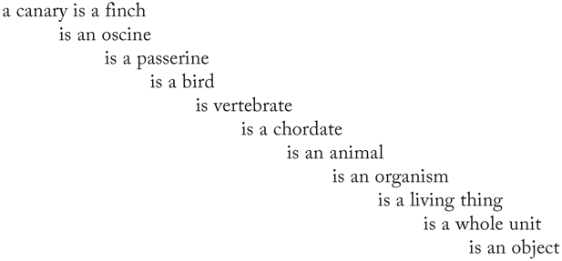

但*canary*本身也有一个下义词，“common canary”（普通金丝雀）。如果你以为我可以让金丝雀歇歇了，那么*canary*还有一系列姊妹词，从*goldfinch*（金翅雀）到*crossbill*（交嘴雀）、*bullfinch*（红腹灰雀）、*cardinal*（红衣凤头鸟）、*honeycreeper*（旋蜜雀），以及几十种其他长羽毛的朋友。

But *canary* also has a hyponym itself, the “common canary.” And if you thought I could put the canary to rest, *canary* also has a range of sister terms from *goldfinch* to *crossbill*, *bullfinch*, *cardinal*, *honeycreeper*, and dozens of other feathery friends.

WordNet已被证明是计算机科学家的一个绝佳资源。例如，WordNet被用于IBM的沃森（Watson），这是一个问答计算机系统，允许用户用自然语言提问。然后沃森作出回答。2011年，沃森击败了《危险边缘》（*Jeopardy!*）的冠军布拉德·鲁特和肯·詹宁斯，赢得了一百万美元的头奖。你可以想象，要让计算机回答一个《危险边缘》的问题，系统需要通过考虑一个词的所有语义关系来理解这个词，才能得出答案。而像WordNet这样的语义网络的计算实现可以提供帮助。

WordNet has proven to be a great resource for computer scientists. For instance, WordNet has been used for IBM Watson, a question-answering computer system that allows its users to ask questions in natural language. Watson then answers back. In 2011 Watson beat *Jeopardy!* champions Brad Rutter and Ken Jennings and won the first prize of $1 million. You can imagine that for a computer to answer a *Jeopardy!* question, the system needs to understand a word by taking all its semantic relations into account in order to come up with an answer. And a computational implementation of a semantic network like WordNet can be of help.

而这些还只是单个的词。正如前面所论证的，说到语言，我们几乎从不孤立地、脱离语境地使用词语。认知心理学家沃尔特·金奇和篇章语言学家特恩·范戴克对此再清楚不过。<sup>9</sup>他们试图构建一个句子意义的抽象。这样的抽象是必要的。很难把“金丝雀”这一概念想成宠物店里的某只特定金丝雀、我邻居家的金丝雀、我在女儿图画书里看到的金丝雀，以及我在华纳兄弟动画片里看到的金丝雀；语义网络是由所有这些具体金丝雀的抽象组成的。

And these are just single words. And as argued before, when it comes to language, we hardly ever use words in isolation, out of context. Cognitive psychologist Walter Kintsch and text linguist Teun van Dijk understood this all too well.<sup>9</sup> They tried to build an abstraction of the meaning of a sentence. Such an abstraction was needed. It is difficult to think of the concept canary as a specific canary in the pet store, the canary in my neighbor’s house, the canary I saw in my daughter’s picture book, and the canary I saw in the Warner Brothers cartoon; the semantic network consists of an abstraction of all those specific canaries.

类似地，很难把句子“Juliet was kissed by Romeo”（朱丽叶被罗密欧亲吻了）、“Romeo kissed Juliet”（罗密欧亲吻了朱丽叶）、“A kissing took place between Romeo and Juliet”（罗密欧与朱丽叶之间发生了亲吻）、“It was Romeo who kissed Juliet”（是罗密欧亲吻了朱丽叶）想成有不同的意义。就像金丝雀的各个实例有一个公分母一样，更容易的是为罗密欧对朱丽叶所做的亲吻事件想出一个公分母。类似于KISSING (ROMEO, JULIET)（亲吻（罗密欧，朱丽叶））这样的东西。句子的这些抽象被称为命题。因此，一个故事或一篇文本可以表示为一个命题网络。通过使用这些命题网络，范戴克和金奇得以深入了解人类如何理解文本、如何记住文本的要点（他们回忆起最重要的命题），以及我们如何概括文本。

Similarly, it is difficult to think of different meanings of the sentence “Juliet was kissed by Romeo,” “Romeo kissed Juliet,” “A kissing took place between Romeo and Juliet,” “It was Romeo who kissed Juliet.” As with the common denominator of the instances of canary, it’s easier to think about a common denominator for the kissing event done by Romeo to Juliet. Something like KISSING (ROMEO, JULIET). These abstractions of sentences were called propositions. A story or text could thus be presented like a propositional network. And by using these propositional networks, van Dijk and Kintsch were able to get insight in how humans understand texts, how they remember the gist of the text (they recall the most important propositions), and how we summarize text.

随着WordNet的成功，其他计算语言学工具也涌现出来。FrameNet关注语义框架，它类似于命题，由描述一个事件、关系、物体及其参与者的概念结构组成。<sup>10</sup>还有VerbNet，一个把英语动词的句法模式和语义模式联系起来的数据库。<sup>11</sup>命题以及作为工具的VerbNet和FrameNet的好处在于，它们超越了词的层面。但它们仍然需要人工工作。人类必须解释句子，把这些句子改写成命题，然后在网络中把命题相互联系起来。语言使用者如何如此轻松地理解句子和命题——而计算机却如此困难，要依赖精心编制的数据库——这个问题仍然没有得到回答。

With the success of WordNet, other computational linguistic tools emerged. FrameNet focused on semantic frames, similar to propositions, consisting of a conceptual structure describing an event, relation, object, and the participants in it.<sup>10</sup> And VerbNet, a database of English verbs that links their syntactic and semantic patterns.<sup>11</sup> The advantage of propositions, and VerbNet and FrameNet as tools, is that they moved beyond the word level. But they still required manual work. Humans had to interpret the sentences and rewrite these sentences into propositions, and then link the propositions to one another in a network. The question of how language users understand sentences and propositions so easily—while computers have so much difficulty with it, relying on carefully crafted databases—has not been answered.

但还有另一个问题。在我们对语言的心理表征中，有许多东西并没有在语言中呈现出来。我们以《罗密欧与朱丽叶》为例。罗密欧被放逐后，朱丽叶要嫁给帕里斯伯爵。朱丽叶请求推迟婚期，她的母亲拒绝了。于是她去找劳伦斯修士求助。劳伦斯修士想到了一个办法。他给了朱丽叶一剂药水，能让她陷入假死般的昏迷四十二个小时。修士答应派一名信使去通知罗密欧，罗密欧就可以在朱丽叶醒来时回来。所有这些信息都可以用精心编制、相互关联的命题来表示。但当我们理解这篇文本时，有那么多东西不在文本中而在我们心中，以至于基于命题进行推理是很困难的。例如，我们知道，如果一个人死了，他们就不必嫁给任何人了。或者我们知道，如果有人喝下致命剂量的毒药，他们会立即死去。或者，如果一个人相信他一生的挚爱刚刚死去，他很可能会感到无比的悲伤和绝望。如果有人死了，他们就会一直死着。那么，在文本中没有给出这些信息的情况下，我们是如何知道所有这些信息的呢？

But there was another problem. Much of what is not presented in language is used in our mental representation of the language. Let’s use *Romeo and Juliet* as an example. When Romeo is exiled, Juliet is supposed to marry Count Paris. When Juliet asks to delay the marriage, her mother refuses. She then goes to Friar Laurence and asks for advice. Friar Laurence has an idea. He offers Juliet a potion that will put her into a deathlike coma for forty-two hours. The Friar promises to send a messenger to inform Romeo, who can then return when Juliet awakens. All this information can be presented in carefully crafted propositions that are interconnected. But when we understand this text, there is so much that is not in the text, but is in our mind, that making inferences based on propositions is hard. For instance, we know that if a person were dead, they would not have to marry anyone. Or we know that if someone drinks a fatal dose of poison, they immediately die. Or that if one believes that the love of his life has just died, then he is likely to feel overwhelming sadness and hopelessness. That if someone dies, they stay dead. So how do we know all these pieces of information, without them being given in the text?

心理学家一直在为这个问题苦恼，但对计算机科学家来说，这个问题同样难以回答。像WordNet这样的项目非常适合开发一个词的语义网络，但你如何处理常识信息、处理推理呢？计算机如何才能像人一样推理？大约在乔治·米勒启动WordNet来描绘词的意义的同时，道格拉斯·莱纳特开始了一个雄心勃勃的项目，要把构成人类常识的数百万条知识编码起来。这个项目被称为Cyc，它是一个推理引擎和一个陈述数据库。<sup>12</sup>所有这些知识都是由一支人类监督员团队录入的。时至今日，已有超过2500万条这样的一般规则被编码并形式化地表示出来。

Psychologists have struggled with this question, but for a computer scientist, this question was equally difficult to answer. An initiative like Word-Net is great to develop a semantic network of words, but how do you deal with commonsense information, inferences? How could a computer reason like a human? Around the time George Miller started WordNet to map out the meaning of words, Douglas Lenat began an ambitious project to code the millions of pieces of knowledge that make up human common sense. The project was dubbed Cyc and is an inference engine and a database of statements.<sup>12</sup> All these pieces of knowledge were entered by a staff of human supervisors. As of today, over 25 million such general rules have been codified and formally represented.

所以，如果你问这样一个问题：“当朱丽叶服下假死药时，她是否相信在她处于假死状态期间，罗密欧会相信她是活着的？”Cyc会回答：

So if you ask the question “When she takes the feign-death potion, does Juliet believe Romeo will believe she is alive during the time she is in suspension?” Cyc will answer:

> 是的。如果在时刻T1，一个主体对某个对象在时刻T2的信念的模型中包含一个命题，那么该主体在T1相信该对象在T2相信这个命题。

> Yes. If, at time T1, an agent’s model of a subject’s beliefs at time T2 includes a proposition, then the agent believes at T1 that the subject believes the proposition at T2.

> 在朱丽叶服下假死药的时刻，朱丽叶对罗密欧在朱丽叶服药后处于假死状态期间的信念有一个模型，这个模型包含“朱丽叶是一个活物”这一命题。<sup>13</sup>

> At the time of Juliet’s taking of the feign-death potion, Juliet has a model of Romeo’s beliefs at the time of Juliet’s being in suspension after taking the feign-death potion that includes the proposition that Juliet is a living thing.<sup>13</sup>

尽管Cyc是一个不可思议的常识知识库，我们还是可以问：为什么要一个由许许多多编码员组成的团队花三十五年时间来实现2500万条常识规则，而其中许多规则对任何一个孩子来说都是自然而然的？

Even though Cyc is an incredible repository of common knowledge, we can ask why it takes a team of many, many coders thirty-five years to implement 25 million commonsense rules, many of which come naturally to any child.

那么，无论语义网络是层级的，无论某些词是否比其他词更具原型性，无论我们在想到一个词时心中是否有特征列表，或者语义网络是否只是大量相互连接的单元的集合，真正的问题是它们是如何产生的。WordNet花了多年的人工工作来找出词与词之间的许多语义关系。而WordNet只看词，甚至不看句子。Cyc确实超越了句子，但仍然需要大批监督员团队花多年时间录入信息。而我们这些热衷的语言使用者，并不需要任何人工工作就能理解词与词、句与句之间的关系，以及我们基于这些词和句子所作的推理。这对我们来说是自然而然的。我们是如何把那些词记在心里的？

Now whether a semantic network is hierarchical, whether some words are more prototypical than others, whether we have lists of features in our mind when thinking about a word, or whether semantic networks are simply a large collection of interconnected units, the real question is how they come about. WordNet has taken years of manual work identifying the many semantic relations between the words. And WordNet only looks at words, not even sentences. Cyc does move beyond sentences, but still has required large teams of supervisors entering information for years. And we, avid language users, do not require any manual work to understand the relationships between words and sentences, and the inferences we make on the basis of those words and sentences. It comes naturally to us. How do we keep those words in mind?

## 神经网络

## NEURAL NETWORKS

也许要回答语义网络是如何运作的，我们需要更深入地观察人脑。在上一章中，我们从半球和语言区的角度观察了大脑，但也许我们应该再深入一点，以便更好地理解这些区域内部发生了什么。

Perhaps for an answer to how semantic networks operate, we need to look deeper at the human brain. In the previous chapter, we looked at the brain in terms of hemispheres and language areas, but perhaps we should dig a little deeper into the brain to better understand what is happening within these areas.

人脑由大约1000亿个被称为神经元的生物细胞组成。这些神经元负责大脑中信息的传递和保持。它们看起来有点像一棵有树干和树枝的树。神经元的这些“树枝”被称为树突（源自希腊语中的“树”一词），从其他神经元接收信息。每个神经元与大约一千个其他神经元相连。你只能想象一个有一万亿个连接的不可思议的网络是什么样子。这个庞大的神经网络有相当多的好处。

The human brain consists of some 100 billion biological cells, called neurons. These neurons are responsible for the transmission and retention of information in the brain. They look a bit like a tree with a stem and branches. These “branches” of neurons are called dendrites (from the Greek word *tree*) and receive information from other neurons. Every neuron is connected to some one thousand other neurons. You can only imagine what an incredible network of 1 trillion connections looks like. That massive neural network has quite some benefits.

我们的思维似乎极其迅速。在第2章（“语言”）中，我已经讨论过我们加工语言有多快，但有人可以认为，从一页纸上捕捉词语或从言语中捕捉声音本身就需要一些时间。思维的过程——在字母投射到我们的视网膜上、或声音击中我们耳朵的毛细胞之后——似乎进行得更快。想一想，我能以光速想出一千个念头，至少看起来是这样。神经元中信息传递的速度随神经元的粗细而变化。有些神经元的传递速度在每小时150到250英里之间，而另一些只有每小时一到四英里。但即使是每小时150–250英里，与光速相比也相当慢了，光速大约是每小时670,000,000英里！

Our thoughts seem to go extremely fast. In chapter 2 (“Language”), I already discussed how fast we process language, but one can argue that picking up the words from a page or picking up the sounds from speech takes up some time in itself. The process of thinking—after the letters projected onto our retina or the sounds that have hit our ears’ hair cells—seems to go even faster. Thinking about it, I can think a thousand thoughts with the speed of light, at least so it seems. The speed with which information in neurons travels varies in speed as a consequence of the width of the neuron. Some neurons travel between 150 and 250 miles an hour, while others make it to only one to four miles an hour. But even the 150–250 miles an hour is rather slow, when compared to the speed of light, light traveling about 670,000,000 miles per hour!

当然，传递的距离会有影响。例如，一个信号需要传递的距离决定了它的反应时间（你手的动作比你脚的动作快）。但在更大的尺度上，这一点更是如此。一个信号在你大脑中传递的距离，比光在宇宙中需要传递的距离要小得多。但我的思维*似乎*能跟上光速，还有另一个原因，这个原因对于大脑的神经网络以及我们加工语言的方式都很重要。

Now the distance traveled, of course, makes a difference. For instance, the distance a signal needs to travel determines its reaction time (the movements of your hand are faster than the movements of your foot). But on a larger scale, this is even more true. The distance a signal travels within your brain is considerably smaller than the distance lights need to travel in the universe. But there is another reason my thoughts *seem* to keep up with the speed of light, and that reason is important for the brain’s neural network as well as for the way we process language.

如果大脑是一步一步地加工信息，速度就很重要。如果我们的神经元像多米诺骨牌挑战那样工作，一块接一块地推倒骨牌，这个过程会相当缓慢。一个神经元接着一个神经元放电的序列，会使我在想着自己的狗时无法读出*dog*这个词。但与计算机的工作方式不同，大脑的神经元不是串行地、一步一步地发送信号，而是并行地发送。把它与流感的爆发作比较。并不是我得了流感打个喷嚏，就有另一个人得流感，她打喷嚏时再把病毒传下去，如此等等，形成一条长长的病毒传播链。正如我们在COVID-19病毒的传播中体会得再清楚不过的那样，一个人可能同时感染十个人，而这些人——不必彼此等待——又把病毒传播得更远，形成一个大范围的病毒激活模式。回到大脑：大脑中有一万亿个连接，一个信号可以同时在这些连接上传递。信号传递的速度并不那么重要，重要的是并行激活的扩散。

If the brain were to process information step by step, speed matters. If our neurons were to work like a domino challenge, toppling one domino stone after the other, the process would be rather slow. The sequence of one neuron firing to the next one would make it impossible to read the word *dog* while thinking about my own dog. But in contrast to the way computers work, the brain’s neurons do not send signals in serial, step by step, but in parallel. Compare it with the outbreak of the flu. It is not the case that when I have the flu and sneeze, one other person gets the flu, who passes the virus on when she sneezes, and so on, resulting in one large chain of virus spreaders. As we have experienced all too well with the spreading of the COVID-19 virus, one person might infect ten others simultaneously, who—not waiting for one another—spread the virus even further, resulting in a large pattern of virus activation. But back to the brain: with the trillion connections in the brain, a signal can travel across these connections simultaneously. The speed with which a signal travels is not that important, but the spread of parallel activation is.

当我说神经元把信息发放给其他神经元时，人们很容易认为一个神经元容纳了一个完整的概念。一个保存着我对祖母记忆的“祖母细胞”。或者一个比如在播放电视剧《老友记》（*Friends*）时就会放电的“詹妮弗·安妮斯顿神经元”。尽管有人针对特定类型的加工（例如面孔识别）主张过祖母细胞或詹妮弗·安妮斯顿神经元的存在，<sup>14</sup>但总体而言，神经元“容纳”信息的想法是一种误解。不存在“金丝雀”神经元，也不存在“黄色”神经元和“飞”神经元。相反，在神经元中传递的电信号是一种全或无的信号。神经元要么放电，要么不放电。我们所理解的那种信息，比如“金丝雀”这一概念，不是一个神经元中的信息，而是在一个网络中活跃的一群神经元之间的激活模式。所以金丝雀在大脑中可能被表示为101011011011——的确，就像计算机代码一样，在你的硬盘上，一个概念也是以*1*和*0*的序列存储的。至少对于神经元的电信号是这样，对于化学信号则不尽然。化学信号是分级的，并且在神经元之间连接处——即突触——流动的神经递质中是可以调节的。<sup>15</sup>

When I say that neurons fire information to other neurons, it is tempting to think one neuron holds an entire concept. A grandmother cell that holds the memories of my grandmother. Or a Jennifer Aniston neuron that, for example, fires when the *Friends* television series is shown. Although the argument has been made for a grandmother cell or Jennifer Aniston neuron<sup>14</sup> for specific kinds of processing, for instance, in the case of facial recognition, overall the idea of holding information is a misconception. There is no “canary” neuron, or a “yellow” and “fly” neuron. Instead, the electrical signal that travels through a neuron is an all-or-nothing signal. The neuron fires, or it does not. Information the way we understand it, such as the concept of “canary,” is not the information in one neuron but a pattern of activation across a bunch of neurons that are active in a network. So canaries in the brain may be represented as 101011011011—indeed, like computer code, where a concept is also stored on your hard drive as a sequence of *1*s and *0*s. This is at least true for the electrical signal of neurons, not quite for the chemical signal. The chemical signals are graded and modifiable in the neurotransmitters that flow between the connections between neurons, the synapses.<sup>15</sup>

## 一堆沙子

## PILE OF SAND

现在让我们更仔细地看看网络中的神经元是如何运作的，以便更好地理解大脑中神经网络的功能，以及它在计算机中的人工版本的开发。为了向你介绍神经网络的世界，让我用一堆沙子来说明。没错，我在拿你的大脑和一堆沙子作比较。只是打个比方。

Now let’s have a closer look at the way neurons in a network operate, in order to better understand the functioning of a neural network in the brain, and the developing of an artificial version of it in computers. To introduce you to the world of neural networks, let me illustrate with a pile of sand. That’s right, I am comparing your brain to a pile of sand. Just as an analogy.

当你把水倒在一堆沙子上时，水会流向四面八方。还没有任何通道决定水如何流过沙堆，但第二次往沙堆上倒水时，情况就变了。这时开始形成一些最初的沟渠。水可能仍会在沟渠之间溢出，但已经不再是流向所有可能的方向了。相反，它开始被引入沟渠。往沙堆上倒的水越多，水就把沟渠冲得越深。在沟渠之间溢出的水越来越少，水也更快地流到沙堆的底部。

When you pour water on the pile of sand, the water flows in all directions. There are no pathways yet that determine how the water flows over the pile, but this changes the second time you pour water over the pile. Then some initial channels start to form. Water might still spill between channels, but it is not the case that water flows in all possible directions any longer. Instead, it starts to be canalized. The more water is poured over the pile of sand, the more the water deepens the channels. There is less water being spilled across channels, and water finds its way more quickly to the end of the pile.

这个比喻说明了几件事。起初，沙堆中并没有真正的连接（没有任何沟渠），但随着时间推移，沙堆“学会”了哪些沟渠来引水，以及沟渠需要多深。此外，水起初流向许多不同的方向，而当沟渠形成后，水就高效而迅速地流到沟渠的尽头。沟渠越深，沙堆就越学会如何分配水。最后，如果沙堆中的一条水渠被堵住了，水会利用其他沟渠流到沙堆的底部。并不是水流停止了，或者沙堆坍塌了，而是水流找到了在沟渠上分配自身的新方式，沟渠的深度会随着水对它们的利用而调整。

This analogy shows a few things. At first, there are not really any connections (any channels) in the pile of sand, but over time the pile of sand “learns” which channels carry the water and how deep the channels need to be. Moreover, whereas water initially is flowing in many different directions, when channels are formed, the water flows efficiently and quickly to the end of the channel. The deeper the channel, the more the pile of sand has learned how to distribute the water. And finally, if one of the water channels in the pile of sand gets blocked, the water will make use of other channels to get to the bottom of the pile. It’s not that the flow of water stops, or the pile of sand breaks down, but that the flow of water finds new ways of distributing itself over channels, with the depths of the channels adjusting as a function of water making use of them.

现在想象一下，你倒在沙堆上的水有不同的颜色。有一瓶蓝色的水，一瓶红色的水，还有一瓶黄色的水。任何一个拿过涂色本的孩子都知道，蓝色和黄色混合成绿色，蓝色、黄色和红色混合成棕色。但颜色的混合取决于两件事：你倒入混合物中的颜色的量，以及你倒入混合物中的颜色本身。在我们的沙堆例子中，这取决于你往沙堆上倒了多少黄瓶或蓝瓶的水，也取决于沟渠有多深。某种颜色的有色水越多，其流经的沟渠越深，这种颜色就比流经不太深的沟渠的颜色更突出（黄色太多，你就会得到非常浅的绿色）。现在汇合在一起的沟渠决定了结果。也就是说，蓝色和黄色的染料会得到绿色，但如果这些沟渠与红色混合，你就会得到棕色。所以沟渠的深度（沟渠有多宽多深）和有色水的量（一勺还是两勺）决定了沙堆上水的输出（或者我应该说流出）。

Now imagine that the water you pour over the pile of sand consists of different colors. There is one bottle with blue water, a bottle of red water, and a bottle of yellow water. As any child with a coloring book knows, blue and yellow mix to a green color, and blue, yellow, and red to a brown color. But the mix of colors depends on two things: the amount of color you pour into the mix, and the colors themselves you pour into the mix. In our pile of sand example, it depends how much of the yellow bottle or the blue bottle you pour over the pile, but also how deep the channels are. More colored water of one color with a channel that runs deeper will have more a prominence for a particular color than channels that do not run too deep (too much yellow, and you will get very light green). Now the channels that come together determine the outcome. That is, blue and yellow dye will give green, but if these channels mix with red, you get brown. So the depth of the channel (how wide and deep a channel is) and the amount of dyed water (one spoonful or two spoonfuls) matter in the output (or should I say outpour) of the water on the pile of sand.

还跟得上吗？现在我们把有色水的量称为“输入单元”。我们有蓝色、黄色和红色的水，所以有三个输入单元。我们把沟渠的深度和宽度称为“权重”。如果有色水流过一条沟渠，那么输入单元就有一个权重，在我们的例子中是三个输入单元，各有自己的权重。现在假设（由有色水）形成的颜色称为激活。我们现在可以说，输出单元（最终的颜色）的激活总和，是由所有输入到它的单元（三种颜色）以及权重（沟渠的深度和宽度）的总和决定的。

Still with me? Now let’s call the amount of dyed water “input unit.” We have blue, yellow, and red water, so three input units. And let’s call the depth and width of the channels “weights.” If dyed water runs through a channel, the input unit thus has a weight, in our example three input units each with their own weights. Now let’s say that the color that is formed (by the dyed colors) is called the activation. We can now say that the sum of activation of the output unit (the final color) is determined by the sum of all the units that input to it (the three colors) and the weights (the channel depth and width).

如果有色水的量和沙堆中沟渠的深度是预先确定的，得到绿色就相对容易。但神经网络的魔力在于，它们完全靠自己学会需要多少有色水、沟渠需要多深。它们做到这一点的方式是向系统提供反馈，这个过程被称为*反向传播*（back-propagation）。起初，我们只是把有色水倒在沙堆上，不在乎倒了多少黄水、蓝水和红水。沟渠的深度也各不相同。在沙堆的底部，我们把得到的颜色与理想的绿色进行比较。如果不匹配，就计算出我们得到的和我们想要的之间的误差，并相应地调整沟渠（给连接施加权重）。最终，经过足够的训练，完美的绿色就会顺着沙堆流下来。下次我们往沙堆上倒有色水时，就会得到系统受训所得的那种颜色。

If the amount of dyed water and the depth of the channels in the pile of sand were to be predetermined, it is relatively easy to obtain a green color. But the magic of neural networks is that they learn how much dyed water and how deep the channels need to be entirely by themselves. The way they do this is by providing feedback into the system, a process that is called *back-propagation*. Initially, we just pour dyed water onto the pile of sand, not taking care how much yellow, blue, and red water we pour down. The channels also differ in depth. At the end of the pile of sand, we compare the color that is obtained with an ideal color green. If there is a mismatch, the error gets computed between what we got and what we wanted to have, and we adjust the channel accordingly (apply weights to the connections). Ultimately, after enough training, the perfect color green runs down the pile of sand. Next time we pour dyed water over the pile of sand, we obtain the color that the system was trained on.

神经网络与沙堆之间的类比有很多不成立的地方。但我希望这个例子至少能帮助理解两件事。首先，这个例子应该能帮助你理解，我们可以从一块白板开始——一堆从未被浇过水的沙子。随着时间推移，系统会根据流经沙堆系统的数据——水——学会如何形成模式——沟渠。网络的权重根据流经网络的信息而调整。这使得神经网络相当强大。你不必一直告诉网络什么是对的、什么是错的；相反，在训练阶段，网络被告知什么是对的、什么是错的（“不对，这变得太棕了！”“不不，绿色有点太浅了！”“不，还不太对，现在绿色太深了！”），但之后它就能够自己学习了。即使它得到了新的信息，比如一种新的颜色，它也能根据学到的规则自己作出决定。

There are many reasons why the analogy between a neural network and a pile of sand does not work. But I hope this example helps in understanding at least two things. First of all, the example is supposed to help you understand that we can start out with a blank slate—a pile of sand that has never had any water poured over it. Over time the system learns how patterns—channels—are formed based on the data—the water—sent through the pile of sand system. The weights of the network get adjusted based on the information that flows through the network. And that makes neural network pretty powerful. You do not have to continuously tell the network what is right and what is wrong; instead, in a training phase the network is told what is right and what is wrong (“No, this becomes too brown!” “No, no, the green is a little too light!” “No, not quite, now the green is too dark!”) but is then able to learn by itself. Even if it gets new information, for instance a new color, based on the rules it has learned it is able to make its own decisions.

我也希望沙堆的例子有助于理解系统——我们的沙堆——是如何把信息分布在网络——所形成的水渠——上的。流经网络的数据越多，沟渠就变得越强。这意味着，即使你往沙堆上倒的有色水太少或太多，你也许仍然能够恢复出绿色。事实上，即使有人过来堵住了沙堆上的一些沟渠，系统也不会崩溃，而是会重新分配信息，加强已经形成的沟渠。其他沟渠现在可以接管过来，仍然把水的颜色带到输出的颜色中。

I also hope the pile of sand example helps in understanding how the system—our pile of sand—distributes information over the network—the channels of water that are formed. The more data that is sent through the network, the stronger the channels become. That means that if you pour too little or too much dyed water over the pile of sand, you might still be able to recover the green color. In fact, even if somebody comes along and blocks some of the channels on the pile of sand, the system does not collapse, but redistributes the information, strengthening the channels that have been formed already. Other channels may now take over and still carry the colors of the water through to the output color.

## 人工神经网络

## ARTIFICIAL NEURAL NETWORKS

神经网络存在于大脑中。但我们也可以在计算机中重建它们。这些人工神经网络，或者说联结主义模型，基本上以与人脑中的神经网络相同的方式工作。有输入单元（在我们的沙堆类比中是蓝色、黄色和红色）和输出单元（在我们的类比中是绿色）。形成的沟渠有分支。每出现一组新的分支，我们就可以识别出一层。简单的神经网络只有一两层，但更复杂的神经网络有许多不同的层，即所谓的隐藏层。这些隐藏层把信息分布在各条通道上，从而使网络中的激活模式形成信息。

Neural networks are in the brain. But we can also recreate them in a computer. These artificial neural networks, or connectionist models, basically work the same way as the neural network in the human brain. There are input units (in our pile of sand analogy the blue, yellow, and red color) and output units (in our analogy the green color). The channels that are formed have branches. Each time there is a new collection of branches, we can identify a layer. Simple neural networks only have one or two layers, but more sophisticated neural networks have many different layers, so-called hidden layers. These hidden layers distribute information over channels, so that patterns of activation in the network form information.

神经网络，特别是人工神经网络，从20世纪50年代到90年代极其流行。“控制论”（Cybernetics）——人工网络在20世纪40年代至60年代的叫法——随着第一批问世的计算机而大受欢迎。20世纪80年代至90年代的“联结主义”（Connectionism）引发了热潮，因为计算机似乎真的在模仿人脑。无论是识别图片、理解手写体还是进行语音识别，神经网络都是答案！

Neural networks, and particularly artificial neural networks, were extremely popular from the 1950s through the 1990s. “Cybernetics,” as artificial networks were called in the 1940s–1960s, were very popular with the first computers to see daylight. “Connectionism” in the 1980s–1990s triggered enthusiasm as computers really seemed to mimic the human brain. Whether it concerned recognizing pictures, understanding handwriting, or performing speech recognition, neural networks were the answer!

它们似乎也极其强大，这是我在读博士期间发现的。当我自己试验人工神经网络时，我决心弄清楚自己能否生成故事的摘要。我收集了若干故事及其摘要，训练了一个大型神经网络来概括这些故事。一些初步测试效果相当好，所以我很兴奋。因为我知道这个网络会占用大量计算资源，我决定最保险的做法是在星期五晚上开始运行分析，让它整个周末都运行着。我一启动网络，激活单元就亮了起来，激活模式在网络中传送。这些五彩缤纷的烟花本身就值得运行这次分析了！那时候你还得拨号上网，所以我无法持续在线监控网络的进展。

They also seemed to be extremely powerful, as I found out during my PhD studies. When I was experimenting with artificial neural networks myself, I was determined to find out whether I would be able to create summaries of stories. I had collected several stories and their summaries and trained a large neural network to summarize the stories. Some initial tests worked pretty well, so I was excited. Because I knew that the network would take up a lot of computing power, I decided it was safest to start running my analyses on Friday night and have it run throughout the weekend. As soon as I started running the network, the activation units lit up, and patterns of activation were sent through the network. These colorful fireworks in themselves were worth running the analysis! These were the days that you had to dial in to the internet, so I would not be able to consistently monitor the network’s progress online.

星期一早上，我骑上自行车去校园，满心希望能找到一些非常酷的结果。系里的IT专家迎面走来，他看起来很不高兴。我运行的网络基本上扰乱了所有的互联网流量。它占用了如此多的资源，以至于系里过了好一阵子才恢复正常。但尽管我的分析造成了计算能力的中断，结果看起来还真挺酷的！

Monday morning, I got on my bike and cycled to the campus, hopeful to find some really cool results. I was met by the IT expert in the department, and he did not look happy. The network I ran had basically disrupted all internet traffic. It had taken up so many resources that it took a while before things in the department were back to normal. But despite the computational power outage my analysis had cost, the results looked pretty cool!

第一批神经网络是在20世纪50年代问世的，伴随着大量的兴奋。1958年7月8日的《纽约时报》写道：“海军今天展示了一台电子计算机的胚胎，它预期这台计算机将能够走路、说话、看、写、自我复制，并意识到自己的存在。”与人类胚胎不同，电子计算机的胚胎显然在其生命周期中需要更多的时间，因为七十年后，拥有人工心智的电子胚胎仍然不能走路、说话、看、写、自我复制并意识到自己的存在。<sup>16</sup>但与此同时，人们已经取得了很大的进展。<sup>17</sup>

The first neural networks were introduced in the 1950s, accompanied by a lot of excitement. The July 8, 1958, issue of the *New York Times* stated, “The Navy revealed the embryo of an electronic computer today that it expects will be able to walk, talk, see, write, reproduce itself and be conscious of its existence.” Contrary to human embryos, embryos of electronic computers apparently need more time in their life cycle, as seventy years later the electronic embryos with their artificial minds are not able to walk, talk, see, write, reproduce themselves, and be conscious of their existence.<sup>16</sup> But a lot of progress has been made in the meantime.<sup>17</sup>

提出我们一开始讨论的语义网络的罗斯·奎利恩，就已经强调过语义网络可以被看作神经网络，<sup>18</sup>但直到20世纪80年代，人工神经网络的研究才真正起飞。当我往右边看时，我看到书架上摆着一套两卷本的书：一本蓝色的，一本棕色的。对我来说，这两卷书最好地定义了认知科学领域。书脊上写着《并行分布式加工：认知微结构探索》（*Parallel Distributed Processing: Explorations in the Microstructure of Cognition*），戴维·E. 鲁梅尔哈特、詹姆斯·L. 麦克莱兰与PDP研究小组（PDP代表并行分布式加工）。这部两卷本的书收录了当时（以及如今的许多）所有杰出的联结主义者撰写的章节。它追问是什么让人比计算机更聪明，然后通过描述人脑的大规模并行架构来回答这个问题。这本书不仅奠定了今天所谓深度学习的基础，还提供了知觉、记忆、语言和思维的模型。二十年后，詹姆斯·麦克莱兰把PDP的工作路线扩展到了语义认知。<sup>19</sup>

Ross Quillian, who proposed the semantic networks we started out with, already emphasized that semantic networks could be seen as neural networks,<sup>18</sup> but it took until the 1980s for research in artificial neural networks to really take off. When I look to my right, I see two volumes of a book featured on my bookshelf: a blue one and a brown one. They are the two volumes that for me best define the field of cognitive science. The spines of the books read *Parallel Distributed Processing: Explorations in the Microstructure of Cognition, David E. Rumelhart, James L. McClelland, and the PDP Research Group* (PDP stands for parallel distributed processing). The two-volume book includes chapters by all prominent connectionists at the time (and many of today). It questions what it is that makes people smarter than computers, and then answers this question by describing the massively parallel architecture of the human brain. The book provided not only the foundations of what is called deep learning today but also models of perception, memory, language, and thought. James McClelland extended the line of PDP work for semantic cognition two decades later.<sup>19</sup>

让我们再多看看用于语义认知的这些人工神经网络。通常，这些网络有输入单元——信息从这里进入——和输出单元——信息从这里出来。想象下面这个人工神经网络，它有三个输入单元和一个输出单元。

Let’s look at these artificial neural networks for semantic cognition a bit more. Typically, these networks have input units—where information goes in—and output units—where information comes out. Imagine the following artificial neural network, with three input units and one output unit.

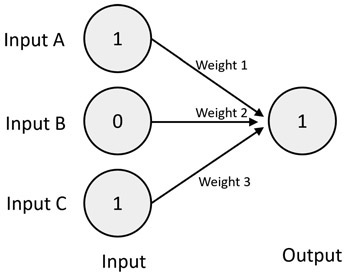

每个单元只能取一个值，1或0，开或关。对于输入的每一种组合——比如1, 1, 0；0, 1, 0；或者如图所示的1, 0, 1——输出可以是0或（如图所示的）1。假设网络的任务是判断一组特征是不是鸟。输入A是这个概念是否有喙（是 = 1，否 = 0），输入B是这个概念是否会飞（是 = 1，否 = 0），输入C是这个概念是否是黄色的（是 = 1，否 = 0）。网络的输出是我们处理的是不是一只鸟（是 = 1，否 = 0）。

Each of these units can only have one value, 1 or 0, on or off. For each of the combinations of the input—for instance, 1, 1, 0; 0, 1, 0; or as depicted, 1, 0, 1—the output can be either 0 or (as depicted) 1. Let’s assume that the network’s task is to determine whether a set of features is a bird or not. Input A is whether or not the concept has a beak (yes = 1 and no = 0), input B is whether or not the concept flies (yes = 1 and no = 0), and input C is whether or not the concept is yellow (yes = 1 and no = 0). The output of the network is whether or not we are dealing with a bird (yes = 1 and no = 0).

网络的魔力始于权重。对于每个输入单元，都有通向输出单元的权重。权重基本上给出了一个输入单元对输出单元的重要性。重要的是，权重可以被调整，这使得网络可以被训练。想象我们遇到了翠迪，我们需要判断翠迪是不是鸟。翠迪有喙，会飞，是黄色的，某个监督者（裁判、老师、父母，或者我们大脑中的小人）或者反向传播告诉我们翠迪是一只鸟。在遇到任何一只鸟之前，权重（权重1、2和3）被设为随机数；每个输入单元的重要性是随机的。但现在我们知道模式1, 1, 1得出1（一只鸟），于是我们可以开始调整最初随机的权重。我们可以强化这些权重，增大它们。所有单元都被证明是重要的。接下来，网络评估一架黄色的飞机。模式0, 1, 1被送入系统，监督者判定这个概念不是鸟。现在可以根据误差调整权重。显然，对于某物是不是鸟来说，*黄色*和*会飞*不如*有喙*重要。权重2和3被下调，权重1被上调。当红雀这个概念被送入系统时，*有喙*和*会飞*被上调，*黄色*被进一步下调。

The magic of the network starts with the weights. For each of the input units, there are weights for the output unit. The weights basically give the importance of an input unit for the output unit. Importantly, the weights can be adjusted, and this allows for the network to be trained. Imagine that we encounter Tweety, and we need to determine whether Tweety is a bird or not. Tweety has a beak, flies, and is yellow, and some supervisor (a judge, teacher, parent, or homunculus in our brains) or backpropagation tells us that Tweety is a bird. Before ever having encountered a bird, the weights (weight 1, 2, and 3) are set to a random number; each of the input units are randomly important. But now we know that the pattern 1, 1, 1 yields a 1 (a bird), and we can start adjusting the initially random weights. We can reinforce the weights and increase them. All units turn out to be important. Next, the network evaluates a yellow airplane. The pattern 0, 1, 1 is sent through the system, and the supervisor evaluates the concept as not being a bird. The weights can now be adjusted based on the error. Apparently, *yellow* and *fly* are not as important for something to be a bird as *beak* is. Weights 2 and 3 get downgraded, weight 1 upgraded. When the concept of a redbird is sent through the system, *beak* and *fly* get upgraded, and *yellow* downgraded further.

这种分布式表征的好处是，我们不需要分别为一只会飞的黄色翠迪、一只不会飞的红色翠迪，或者其他六种组合中的任何一种准备一个表征单元，而现在只用三个（可开可关的）单元就能概括所有组合。

The advantage of this distributed representation is that we do not need a representation for a yellow Tweety that can fly, a red Tweety that cannot fly, or any of the other six units we would need, but we can now summarize all combinations in only three units (that can be on or off).

不用说，这是对人工神经网络的过度简化。通常，这些网络有大量的输入单元，以及一系列输出单元。但重要的是，它们在输入单元和输出单元之间还有一些东西。就像我的沙堆类比一样，如果能够形成通道，这些网络通常会变得更高效、更强大。这些通道之所以成为可能，是因为有一层或多层隐藏单元，这些单元既不是输入单元也不是输出单元，而是在后台运作的调节单元；它们是隐藏的。输入单元、隐藏单元和输出单元就像人类中枢神经系统中的感觉神经元、中间神经元和运动神经元。感觉神经元从环境中获取信息；例如，它们“感觉”到你正在为心爱的人拿起一枝玫瑰。运动神经元激活肌肉运动，这样每当你的感觉神经元感觉到你拿起的玫瑰茎上有刺时，你的手就会猛地缩回。你的感觉神经元和运动神经元经过训练，使得每当在输入中感觉到尖锐的东西时，输出就是猛地缩回。那么中间神经元呢？中间神经元位于感觉神经元和运动神经元之间，在中枢神经系统中在它们之间传递信息。

Needless to say, this is an oversimplification of an artificial neural network. Typically, these networks have a large number of input units as well as a series of output units. But importantly, they have something in between input and output units. As with my analogy of the pile of sand, these networks generally become more efficient and more powerful if pathways can be formed. These pathways become possible through one or more layers of hidden units, units that are neither input nor output units but moderating units that operate in the background; they are hidden. The input, hidden, and output units are like the sensory neurons, interneurons, and motor neurons in the human central nervous system. The sensory neurons pick up information from the environment; for instance, they “feel” you are picking up a rose for your loved one. The motor neurons activate muscle movements so that your hand jerks away whenever your sensory neurons feel a thorn on the stem of the rose you are picking up. Your sensory neurons and motor neurons are trained so that whenever something sharp is felt in the input, the output is a jerking away. What about the interneurons then? The interneurons sit between the sensory and motor neurons and communicate information between them in the central nervous system.

这看起来可能是一个相当低效的系统。进化显然还没有完全完成它的进程。毕竟，人们会希望，如果拿起了什么非常尖锐的东西，就会立即向运动神经元发出一条信息，让它扔掉所拿的东西。

It may seem this is a rather inefficient system. Evolution apparently has not quite taken its course. After all, one would hope that if something really sharp is picked up, an immediate message is sent out to the motor neurons to drop whatever is picked up.

结果恰恰相反。网络中有了这些中间神经元，就出现了大得多的灵活性和效率。如果你感觉到什么尖锐或滚烫的东西，这可能是一个让你扔掉它的信号——比如在碰到一块碎玻璃或从炉子上拿起一个热锅时。但在许多情况下，是否应该扔掉所拿的东西要视情况而定。如果没有中间神经元，你家附近星巴克的地板就会一塌糊涂。

The opposite turns out to be true. By having these interneurons in the network, far more flexibility and efficiency emerge. If you feel something sharp or hot, it may be a signal to drop it—for instance, when touching a piece of broken glass or picking up a hot pan from the stove. But in many cases, it depends whether one should drop what is being picked up. Without interneurons, the floor of your local Starbucks would be a complete mess.

所以一个更复杂的人工神经网络——但仍然是过度简化的——看起来就像下面呈现的这个。它有三个输入单元、四个隐藏单元和两个输出单元。不出所料，它有多得多的机会在网络中形成激活通道。拥有这些隐藏单元有若干好处，包括不会把热咖啡洒得满地都是。想象一些输入信息有缺陷；比如说，我们从背后观察翠迪，她掉进了一罐红油漆里，结果飞不起来了。因为通道已经形成，我们也许仍然能够识别出翠迪是一只鸟。或者以字符识别为例：网络可能是在*a*、*b*、*c*、*d*……*x*、*y*和*z*上训练的。但现在*a*看起来像*ą*，因此无法被识别。*ąpple*这个词现在成了一个未知的无意义词。然而，多亏了基于输入形成的通道，网络也许能够重建出*apple*（苹果）这个词。

So a more sophisticated artificial neural network—but still an oversimplification—looks like the one presented below. It has three input units, four hidden units, and two output units. Unsurprisingly, it has far more opportunities to form activation pathways through the network. There are several advantages of having these hidden units, including not messing up the floor with hot coffee. Imagine that some of the input information is handicapped; say, for example, we observe Tweety from the back, after she fell in a can of red paint, and is consequently unable to fly. Because pathways have already been formed, we might still be able to identify Tweety as a bird. Or take character recognition: The network may be trained on *a*, *b*, *c*, *d* . . . *x*, *y*, and *z*. But now the *a* looks like an *ą* and can thus not be recognized. The word *ąpple* is now an unknown nonsense word. However, thanks to the pathways being formed based on input, the network might be able to reconstruct the word *apple*.

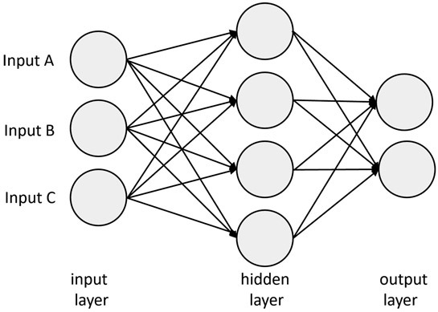

所以让我们把人工神经网络的想法再推进一步，考虑更多的输入单元、更多的隐藏单元和更多的输出单元——以及所有这些单元之间的数千个连接权重。例如，我们可以取一些概念——比如一些树，如松树和橡树；一些花，如玫瑰和雏菊；一些鸟，如知更鸟和金丝雀；以及一些鱼，如太阳鱼和三文鱼。我们还可以列出一系列属性，比如这个概念能否生长、移动、游泳或飞翔，它有没有树皮、花瓣、羽毛或鳞片，以及它是否漂亮、高大、有生命或是红色的。所以我们有一个网络，以概念为输入单元，还有一堆把输入与输出连接起来的隐藏单元。网络要做的，除其他事情外，就是学会金丝雀能移动、生长、飞和游泳。只要我们告诉网络它的激活模式什么时候对了、什么时候错了，它就能学会。目的与其说是弄清金丝雀是不是金丝雀，不如说是测量网络从激活模式的角度学会了“知道”什么。

So let’s take the idea of an artificial neural network even a step further yet and consider more input units, more hidden units, and more output units—and several thousand connection weights between all these units. For instance, we could take some concepts—say, some trees like a pine and an oak, some flowers like a rose and a daisy, some birds like a robin and a canary, and some fish like a sunfish and a salmon. We can also list a series of attributes, like whether the concept can grow, move, swim, or fly, whether it has bark, petals, feathers, or scales, and whether it is pretty, tall, living, or red. So we have a network with concepts as input units and input units with a bunch of hidden units that connect input to output. What the network is supposed to do, among other things, is to learn that canaries can move, grow, fly, and swim. And it can if we tell the network when it got it right in its patterns of activation and when it got it wrong. The purpose is not so much to find out whether a canary is a canary, but to measure what the network learns to “know” in terms of activation patterns.

连接权重根据这种反馈逐渐调整。所以网络一开始在整个网络中随机激活，“以为”金丝雀会游泳、有鳃，但随着它学到的越来越多，它逐渐发现鸟和鱼是彼此不同的。这些激活模式的发展对语义认知很有意义。例如，我们知道，儿童先习得较大的语义区分，然后这些区分才变得更加精细。所以当一个孩子大约八个月大时，他们能够区分动物和家具，但还不太能区分鱼和鸟，或者桌子和椅子。<sup>20</sup>这些区分是后来才出现的。网络表现出完全相同的发展。网络一开始处于植物、树、鸟和鱼都相似的状态。然后慢慢地但确定无疑地，它把类别分开，先把植物和树与鱼和鸟分开，后来又把植物与树、鱼与鸟分开。直到那时，它才开始在这些类别的每一个内部形成区分。在某种程度上，人工心智的计算发展模仿了儿童心智的认知发展。

The connection weights gradually adjust based on this feedback. So the network starts with random activation throughout the network “thinking” canaries swim and have gills, but gradually the more it learns, it finds out that birds and fish are different from one another. And the advancement of these patterns of activation is of interest to semantic cognition. For instance, we know that children acquire larger semantic distinctions first, before these distinctions become more fine-tuned. So when a child is around eight months old, they can distinguish between animals and furniture, but they are not quite able to make distinctions between fish and birds or tables and chairs.<sup>20</sup> Those distinctions emerge later. Networks show an identical development. The network starts out in a state where plants, trees, birds, and fish are alike. Then slowly but surely it moves categories apart, first the plants and trees away from the fish and birds, but later also the plants from the trees and the fish from the birds. And only then it starts to form distinctions between each of these categories. In a way, the computational development of the artificial mind mimics that of the cognitive development of the child’s mind.

网络还学会了哪些属性对一个概念特别重要，哪些属性知道了有用但不是必须知道的。如果网络知道会飞对“鸟”这一概念非常重要，它也知道羽毛和翅膀往往很重要，比黄色更重要。类似地，网络知道哪些属性对不同的类别重要，就像儿童知道对于食物来说颜色比形状更重要、但对于玩具来说形状比颜色更重要一样。<sup>21</sup>所以大小对植物和树的类别很重要，而对鱼和鸟则不重要；而亮度对动物很重要，对植物则不重要。

The network also learns which attributes are particularly important for a concept and which are useful to know but not necessary to know. If the network knows that flying is very important for the concept of a bird, it also knows that feathers and wings tend to be important, more so than the color yellow. Similarly, the network knows which attributes are important for different categories, just like children know that the color of a food item is more important than its shape, but that shape is more important for toys than color is.<sup>21</sup> So size is important for the category of plants and trees but not for the fish and birds, whereas brightness is important for the animals, but not for the plants.

利用这些网络，我们可以看到引入网络的新属性是如何推广到一个概念或一组概念的特定特征上的。或者我们可以评估，如果网络遭受像痴呆症那样的进行性语义损伤，会发生什么。网络中的具体特征首先消失，接着是较为中间层次的特征。随着时间推移，受损的人工心智逐渐表现出与衰老的人类心智相似的退化。

Using these networks, we can see how new attributes introduced to the network generalize to specific features of a concept or groups of concepts. Or we can evaluate what would happen if the network suffers from progressive semantic impairments like dementia. Specific features in the network disappear first, followed by more intermediate features. Gradually, over time, the damaged artificial mind shows similar deterioration as the aging human mind.

在20世纪80年代，人工神经网络似乎时髦到了极点。搞联结主义很酷。后来到了20世纪90年代，范式发生了转移。也许是因为联结主义似乎对它能做到的事情许诺过多，热情消退了。计算能力和足够数据的可获得性（当时没有足够的大数据）使联结主义成了一种学术练习，几乎没有现实世界的应用。

In the 1980s, artificial neural networks seemed to be as hip as they could be. Doing connectionism was cool. Then in the 1990s, the paradigm shifted. Perhaps because connectionism seemed to be overpromising what it would be able to do, enthusiasm dampened. Computer power and the availability of enough data (there was not enough big data) made connectionism an academic exercise, with little real-world applications.

尽管科学家通常并不以品牌塑造和营销著称，但在神经网络方面，他们做得非常出色。他们把人工神经网络和联结主义重新包装为“深度学习”（deep learning），兴奋之情突然又回来了。如今，关于神经网络、机器学习和强化学习的课程数不胜数。每当你听到*AI*，似乎指的就是*深度学习*。<sup>22</sup>自动驾驶汽车只有借助复杂的深度学习才能运行，其网络是在环境上训练的：什么是道路，什么是不同的道路，什么是交通标志，交通标志如何与行人区分开来？识别智能手机上的指纹要用到深度学习；面部识别的算法也是神经网络。语音识别？神经网络。

Even though scientists are typically not known for their branding and marketing, with regards to neural networks, they did an excellent job. They rebranded artificial neural networks and connectionism as “deep learning,” and suddenly the excitement was back. Today, the number of courses on neural networks, machine learning, and reinforcement learning are countless. Any time you hear *AI*, it seems that what is meant is *deep learning*.<sup>22</sup> Self- driving cars can only operate with sophisticated deep learning whereby networks are trained on the environment: What is a road, What are different roads, What is a traffic sign, and How does a traffic sign distinguish itself from a pedestrian? For recognizing fingerprints on your smart phone, deep learning is used; for facial recognition, again the algorithm is a neural network. Speech recognition? Neural networks.

生物神经网络与人工神经网络很难比较。我们可以从神经元的数量上比较它们。人脑中的860亿个神经元及大约100万亿到1000万亿个突触连接，会胜过那些顶级神经网络的大约1600亿个参数的人工网络。但大小不应该是关键。

It is difficult to compare biological neural networks with artificial neural networks. We could compare them in terms of the number of neurons. The 86 billion neurons in the human brain with some 100–1,000 trillion synaptic connections will outperform artificial networks with some 160 billion parameters for the high-end performing neural networks. But size shouldn’t matter.

人工神经网络的架构也与其生物对应物截然不同。在人工神经网络中，信息从一个隐藏层移到下一个隐藏层，而人脑中的隐藏层几乎算不上层，而是相互连接的神经元构成的广阔维度。

The architecture of an artificial neural network is also very different than the biological counterpart. In artificial neural networks, information moves from one hidden layer to the next, whereas hidden layers in the human brain are hardly layers but vast dimensions of interconnected neurons.

美国诗人詹姆斯·惠特科姆创造了这样一句话：“如果它走起来像鸭子，游起来像鸭子，叫起来也像鸭子，那它一定是只鸭子。”<sup>23</sup>对于人工神经网络，人们也可以这样论证。如果人工神经网络的架构看起来像生物神经网络，训练起来像生物神经网络，表现起来也像生物神经网络，那它一定是生物神经网络。但这个结论下得有点太快了。如果它看起来像鸭子、叫起来像鸭子，但需要电池，那它也许终究不是鸭子。

American poet James Whitcomb coined the phrase “When it walks like a duck and swims like a duck and quacks like a duck, it must be a duck.”<sup>23</sup> For artificial neural networks, one could argue the same. If the architecture of an artificial neural network looks like a biological neural network, it trains like a biological neural network, and it performs like a biological neural network, then it must be a biological neural network. But that conclusion comes a bit too fast. If it looks like a duck, quacks like a duck, but needs batteries, it may not be a duck after all.

在为人工神经网络所提供的机会而赞叹的同时，我一直在纠结的一个主要问题，与其说是关于架构、过程或效率，不如说是关于训练和数据。在人工神经网络和机器学习领域，人们对所谓的强化学习相当热衷。学习通过奖励得到强化。每当系统走在正确的轨道上，你就强化它，或者可能惩罚它。这又把我们带回到了第4章（“训练”），在那一章中我们得出结论，这并不是人类如何学习的全部故事。

One of the main questions I am struggling with while being impressed by the opportunities artificial neural networks provide does not so much concern the architecture, the processes, or the efficiency, but concerns the training and the data. In the field of artificial neural networks and machine learning, there is considerable enthusiasm about what is called reinforcement learning. The learning is reinforced by rewards. Every time the system is on the right track, you reinforce or potentially punish it. And that takes us back to chapter 4 (“Training”), where we concluded that cannot quite be the full story of how humans learn.

但我还有一个相关的、更大的担忧。网络如何知道什么是对的、什么是错的，网络中的单元又是什么？在我前面举的简单例子中，为一个概念给出了十几个特征。好吧，这是个简单的例子。但那么应该定义多少个特征呢？应该为金丝雀给出多少个特征，而这些特征在人类认知中又是从哪里来的呢？

But I have a bigger concern that is related. How does the network know what is right and what is wrong, and what are the units in the network? In the simple example I gave earlier, there are some dozen features given for a concept. Okay, this is a simple example. But how many features should then be defined? How many features should be given for a canary, and where do these features come from in human cognition?

最后，对于人工神经网络来说，单元是随机的还是有结构的并不太重要。在自动图像识别中，无论我训练网络所用的像素是否高度结构化，对网络的运作都没有太大影响。当然，它可能运行得快一点，但到目前为止，还没有报告过其他好处。而人们可以提出这样的问题：对语言来说是否也是如此。

And finally, for artificial neural networks, it does not matter too much whether the units are random or structured. Whether I train the network on whether the pixels in automated image recognition are highly structured or not does not matter too much for the functioning of the network. Sure, it may operate a bit faster, but so far, no other advantages have been reported. And the question can be raised whether the same is true for language.

所以，除了训练和本能之外，也许网络也不是我们如何把那些词记在心里的终极答案。与训练和本能一样，网络无疑是答案的一部分，但不是完整的答案。也许我们应该看得更远。

So in addition to training and instinct, perhaps networks are not the ultimate answer either as to how we keep those words in mind. As with training and instinct, network is undoubtedly part of the answer, but not the complete answer. Perhaps we should look further.

• *7* •

• *7* •

# 具身接地

# Grounding

> 也可以主张，最好为机器配备钱能买到的最好的感觉器官，然后教它理解和说英语。这个过程可以遵循对一个孩子的正常教学。指着东西并给它们命名，等等。同样，我不知道正确的答案是什么，但我认为两种方法都应该尝试。

> It can also be maintained that it is best to provide the machine with the best sense organs that money can buy, and then teach it to understand and speak English. That process could follow the normal teaching of a child. Things would be pointed out and named, etc. Again, I do not know what the right answer is, but I think both approaches should be tried.

> ——艾伦·图灵<sup>1</sup>

> —Alan Turing<sup>1</sup>

*那*个人平静地坐在椅子上，看着面前的桌子。房间很朴素，几乎没有什么家具，只有一把椅子和一张桌子。倒不是说他需要更多的东西，但一个没有窗户、几乎没有家具的房间就是那样——朴素。这个人除了四周的四面墙之外什么也看不到。房间的一侧有一个信箱口，正上方挂着一块大牌子，上面写着*input*（输入）。另一侧的墙上有一个类似的信箱口，清清楚楚地写着*output*（输出）。桌子上，就在坐在椅子上的那个人面前，放着一本账簿。当这个人研究这本账簿时，他发现左栏里有一些中文字符组合。在右栏里他也发现了中文字符组合，但是不同的组合。看起来左边的中文字符组合与右边的组合有某种关系。这个人接到的任务很简单。他要等待一张写有中文字符的纸条通过*input*信箱口递给他。然后他要在账簿左栏中找到正确的中文字符序列及其在右栏中对应的中文字符，把它们写在一张空白纸条上，再放进*output*信箱口。基本上，这个人的工作就是把中文字符序列翻译成其他中文字符序列。他在把中文翻译成中文。唯一的问题是，这个人一个中文字都不会说。他对这门语言一窍不通。他基本上被锁在了一间中文屋里。

*T*he man sat calmly in his chair looking at the table in front of him. The room was sober with very little furniture in it, just a chair and a table. Not that he needed much more, but a room with no windows and very little furniture is just that, sober. The man couldn’t see much more than the four walls around him. One side of the room had a letterbox, with a large sign hanging right above it that read *input*. The other side of the wall had a similar letter box that clearly read *output*. On the table, just in front of the man in the chair, lay a ledger. When the man studied the ledger, he found Chinese character combinations in the left column. In the right column he also found Chinese character combinations, but different ones. It seemed that the Chinese character combinations on the left had something to do with the combinations on the right. The task the man had received was simple. He had to wait for a note with Chinese characters written on it being passed on to him through the *input* letterbox. He then had to find the right sequence of Chinese characters in the left column ledger with the corresponding Chinese characters in the right column, write them down on a blank note, and put them in the *output* letter box. Basically, the man’s job was to translate Chinese character sequences into other Chinese character sequences. He was translating Chinese into Chinese. The only problem was that the man did not speak a word of Chinese. He did not know the language at all. He was essentially locked up in a Chinese room.

这个论证——如今以“中文屋论证”而闻名<sup>2</sup>——是这样的：如果中文屋里的这个人把一串任意的中文符号翻译成另一串任意的中文符号，那么这个人真的理解中文吗？从某种意义上说，这正是一个说中文的人在做的事情，比如在回答问题时。他接收到一个中文问题作为输入，在长时记忆中搜索答案，然后用中文产出一个答案作为输出。但他是否能够像一个以中文为母语的人那样加工中文、用中文回答问题呢？

The argument, now famously called the Chinese room argument,<sup>2</sup> is this: If the man in the Chinese room translates a sequence of arbitrary Chinese symbols into another sequence of arbitrary Chinese symbols, then does the man really understand Chinese? In a way this is what a Chinese speaker does, for instance, when answering a question. He receives a question in Chinese as input, searches through his long-term memory for an answer, and produces an answer in Chinese as output. But is he able to process the Chinese language and answer questions in Chinese just like a native speaker of Chinese does?

我们大多数人都会同意，中文屋里的这个人并没有掌握任何中文知识。这个人只是在不理解的情况下把随机的外文字符翻译成其他随机的外文字符。他接收和产出的符号对他来说全都是希腊文——或者更确切地说，是中文。<sup>3</sup>

Most of us would agree the man in the Chinese room does not capture any knowledge of Chinese. The man just translates random foreign characters into other random foreign characters without understanding. The symbols he receives and produces are all Greek to him, or rather, Chinese.<sup>3</sup>

现在想象一下，把这个例子再往前推进一小步。没有房间，没有人，因此也没有人类心智。取而代之的是一个人工心智。一台计算机。人工心智接收的不是中文字符，而是*1*和*0*的组合。人工心智所做的只是把1011011这样的序列翻译成另一个*1*和*0*的序列，比如001101100。如果你同意中文屋里的这个人一个中文字都不懂，而只是在处理字符，你也就必须同意人工心智只是在处理数字。对于人工心智，我们把这些数字称为*字节*。这个论证——中文屋论证——认为，人工心智无法理解从数字组合到其他数字组合的翻译。因此，无法证明计算机拥有心智。它们永远无法理解语言的意义，因为它们所做的只是把字符翻译成其他字符。所以，如果中文屋里的这个人并没有表现出语言理解，而计算机的运作方式又与中文屋里的这个人非常相似，我们就不得不得出结论：上一章所描述的、关于我们如何把那些词记在心里的网络解释需要被摒弃。因为神经网络恰恰就是这样做的：它们把*1*和*0*的序列翻译成其他*1*和*0*的序列，就像中文屋里的那个人一样。

Now imagine taking this example one tiny step further. There is no room, there is no man, and hence there is no human mind. Instead, there is an artificial mind. A computer. The artificial mind does not receive Chinese characters, but combinations of *1*s and *0*s. All the artificial mind does is translate a sequence of 1011011 into another sequence of *1*s and *0*s, say, 001101100. If you agreed that the man in the Chinese room does not understand a word of Chinese, but instead he is crunching characters, you will also have to agree that the artificial mind is crunching numbers. For the artificial mind, let’s call those numbers *bytes*. The argument—the Chinese room argument—is that artificial minds cannot understand the translation from number combinations into other number combinations. And consequently, computers cannot be shown to have a mind. They can never understand the meaning of language, because all they do is translate characters into other characters. So if the man in the Chinese room does not demonstrate language understanding, and if computers operate much like the man in the Chinese room, we will have to conclude that the network explanation for keeping those words in mind described in the previous chapter needs to be dismissed. Because neural networks do exactly that: they translate sequences of *1*s and *0*s into other sequences of *1*s and *0*s just like the man in the Chinese room does.

中文屋论证可能被理解为计算机不能思考的论证。但这根本不是这个论证要说的。<sup>4</sup>如果把计算机定义为能够进行计算的东西，那么每个人都是一台计算机。因此每台计算机都能思考。相反，这个论证要说的是，以符号操纵为形式的计算——把对中文屋里的人来说毫无意义的中文符号翻译成其他中文符号——并不能保证思维。需要的不只是符号操纵。

The Chinese room argument could be perceived as the argument that computers cannot think. But that’s not at all what the argument is about.<sup>4</sup> If a computer is defined as something that can carry out computations, then every human is a computer. And every computer can thus think. Instead, the argument is that computation in terms of symbol manipulation—the translation from Chinese symbols into other Chinese symbols that are meaningless for the man in the Chinese room—does not guarantee thinking. More is needed than symbol manipulation.

基本上，中文屋论证基于两个主张，一个与意义有关，另一个与模拟有关。中文屋论证关于意义告诉我们的是：规则并不等同于意义。句法并不等同于语义。中文屋里的人完全能够应用规则，正如计算机能够运行程序一样，但这与理解语义内容截然不同。我可以编写这样的计算机代码：如果金丝雀会飞，它们就会移动；或者如果金丝雀睡觉，它们就会跳舞；或者如果金丝雀吠叫，它们就会抛弃。计算机代码完全能够把一只吠叫的金丝雀处理成一只抛弃的金丝雀，但这并不意味着计算机能够理解金丝雀吠叫和抛弃这一概念。类似地，中文屋表明模拟并不等同于复制。它可能模拟了人类心智的认知过程，但这并不意味着它拥有那些认知过程。毕竟，在计算机上模拟消化，与计算机真正消化比萨或啤酒是截然不同的。<sup>5</sup>

Basically, the Chinese room argument is based on two claims, one related to meaning, the other to simulation. What the Chinese room argument tells us about meaning is that rules are not the same as meaning. Syntax is not the same as semantics. The man in the Chinese room is perfectly able to apply rules, as is a computer able to run a program, but this is very different from understanding semantic content. I can write computer code that says that if canaries fly, they move; or if canaries sleep, they dance; or if canaries bark, they abandon. The computer code will be perfectly able to process an occurrence of a barking canary into an abandoning canary, but it does not mean that the computer is able to understand the notion of canaries barking and abandoning. And similarly, the Chinese Room shows that simulation is not the same as duplication. It may simulate the cognitive processes of the human mind, but that would not mean that it has those cognitive processes. The simulation of digestion on a computer would, after all, be very different from a computer actually digesting pizza or beer.<sup>5</sup>

中文屋论证是哲学家约翰·塞尔在1980年提出的一个思想实验。这个论证在这里的要点是提出一个问题：*从语言中提取意义由什么构成？*而按照塞尔的说法，答案并不在于人工神经网络所做的符号操纵。的确，中文屋论证对计算机这种符号操纵系统有着重大的影响。如果中文屋论证成立——我们暂且假设它成立——那么自然语言处理和计算语言学领域，以及人工智能，充其量只能做一些看起来像是把输入信箱口的符号与输出信箱口的符号联系起来的事情，而远远达不到人类语言加工的水平。这也意味着，把计算机作为语言加工的隐喻是有缺陷的，我们从中学不到多少东西。

The Chinese room argument is a thought experiment introduced by the philosopher John Searle in 1980. The point of the argument here is to raise the question, *What constitutes extracting meaning from language?* And, according to Searle, the answer does not lie in the symbol manipulation that artificial neural networks do. Indeed, the Chinese room argument has major consequences for symbol manipulation systems that computers are. If the Chinese room argument is valid, and for now we are going to assume it is, then fields of natural language processing and computational linguistics, as well as artificial intelligence, can at best do something that may look like linking symbols from an input letter box to an output letter box, but would not come close to human language processing. It also means that the computer as a metaphor for language processing is flawed and we would not be able to learn much from it.

除了塞尔之外，还有其他人，比如认知科学家斯蒂文·哈纳德，使用了一个与没有窗户的中文屋类似、但没那么让人幽闭恐惧的类比。想象你到达一个外国，却不会说那个国家的语言。你所拥有的只是一本该国语言的词典，词典用该国语言的其他词来解释词语。有词典可用你也许会感到宽慰，但你所能做的只是把词翻译成其他外语词，而这些外语词又可以被翻译成其他外语词。离开机场时，你在街上看到一块写着你不会说的语言的牌子，在词典里查它的意思，找到一串说不通的符号，再去查它们，又找到另一串说不通的符号。你基本上落入了一个符号旋转木马——类似于中文屋的幽闭狂躁，一个无法逃脱的符号旋转木马。

Others, in addition to Searle, such as the cognitive scientist Stevan Harnad, used a similar, less claustrophobic analogy than a Chinese Room with no windows. Imagine that you arrive in a foreign country not speaking the language of that country. All you have is a dictionary with words of that foreign country that are explained in other words of the language spoken in that foreign country. You can feel relieved having the dictionary to your disposal, but all you can do is translate words into other foreign words, which can be translated into other foreign words. Upon leaving the airport, you see a sign on the street in the language you do not speak, look up its meaning in your dictionary, find a sequence of symbols that do not make sense, look them up, and find another sequence of symbols that do not make sense. You basically end up in a symbolic merry-go-round—similar to the cabin fever of the Chinese Room, an inescapable, symbolic merry-go-round.

需要的是某种能让你摆脱所处循环的东西，而那就是外部世界。任意的符号需要与外部世界中的某种东西接地，词语才能说得通。*dog*这个词的意义不是符号“狗”，也不是序列101110111。相反，*dog*这个词的意义是一只有尾巴的四条腿动物的图像、吠叫的声音、狗的气味、抚摸它的感觉，简而言之，就是对一只狗的知觉模拟。那才是它的意义。

What is needed is something that gets you out of the circularity you are in, and that something is the outside world. The arbitrary symbols need to be grounded to something in the outside world for the words to make sense. The meaning of the word dog is not the symbol 狗 or the sequence 101110111. Instead, the meaning of the word dog is the image of a four-legged animal with a tail, the sound of the barking, the smell of a dog, the petting, in short the perceptual simulations of a dog. That is its meaning.

在17世纪，哲学家勒内·笛卡尔认为心智与身体之间有着明确的区别。心智和身体可能是相连的，但心智的心理过程应被视为与身体的功能截然分开的。意识和自我觉知是心智的一部分，应当与大脑清楚地区分开来。的确，理性的心智是神圣的，独立于身体运作——这几乎类似于几个世纪后的论证，即逻辑计算机可以独立于具身而运作，也类似于“大脑是独立于身体的数字计算装置”这一论证。

In the 1600s, the philosopher René Descartes argued that there is a clear distinction between our mind and our body. Mind and body may be connected, but the mental processes of the mind should be seen as very separate from the functions of the body. Consciousness and self-awareness are part of the mind and should be clearly distinguished from the brain. Indeed, the rational mind was divine and operated independent from the body—almost similar to the argument several centuries later that the logical computer could operate independently from an embodiment, and similar to the argument that the brain is a digital computational device separate from the body.

与这种心智独立于身体的观念——即二元论——相反，二十世纪后期的研究者主张具身认知。在上一章中，我们把词语看作语义网络的一部分，按层级、特征集合、原型或实例、理论或其他方式组织起来。这似乎很管用。我们可以在语义网络中查找*chair*（椅子）这个词，发现椅子是一件家具，有四条腿和一个座面，还有一个供人靠背的支撑，而且椅子有许多实例，比如扶手椅、理发椅、摇椅和轮椅。这构成了我们对椅子的知识。但具身认知的研究者认为，这种颇为计算化的观点完全误解了我们关于椅子的人类知识，因为在那种椅子观念中，概念是非具身的。

In contrast to this notion of a mind separate from a body, or dualism, researchers in the late twentieth century argued in favor of embodied cognition. In the previous chapter, we looked at considering words as part of a semantic network, organized as a hierarchy, as a set of features, as prototypes or instances, as a theory or otherwise. And that seemed to work well. We could look up the word *chair* in our semantic network and find that a chair is a piece of furniture, that it has four legs and a seat, with a support for the person’s back, and that there are many instances of chairs, such as an arm chair, a barber chair, a rocking chair, and a wheelchair. That constitutes our knowledge of a chair. But embodied cognition researchers argue this rather computational view is a complete misconception of the human knowledge we have of a chair because in that notion of chair, the concept is nonembodied.

按照具身认知的解释，*chair*这个词的意义不是语义网络中的东西，无论那个网络是层级式的、原型式的还是特征式的。它也不是一个由*1*和*0*构成金丝雀或椅子概念的神经网络。相反，椅子是一组可供性（affordances），即你可以用椅子做的事情：你可以坐在椅子上，换灯泡时可以站在上面，可以把它当书架或桌子用，可以把它举起来，可以用它砸窗户，如果你看到一条蛇，还可以用它把蛇拨开。这些是我们无需被告知或被教导就知道的关于椅子的事情，但我们之所以碰巧知道这些可供性，是因为我们在现实世界中对*椅子*有过知觉经验。让我再举一个例子来说明：

According to an embodied cognition account, the meaning of the word *chair* is not what is in the semantic network, whether it is hierarchical, prototypical, or feature-like. It is not a neural network where *1*s and *0*s constitute the concept of a canary or a chair. Instead, a chair is the set of affordances, things you can do with a chair: you can sit on a chair, you can use it to stand on when changing a light bulb, you can use it as a bookshelf or a table, you can lift it, you can use it to smash a window, and if you see a snake, you can use it to flick the snake away. These are the things we know about chairs without being told or taught, but these affordances we happen to know because of the perceptual experiences we have with *chair* in the real world. Let me illustrate with another example:

> 想象你有500块砖。如果你从飞机上扔下一块，你还剩几块？我想这个问题的答案并不太难：499块。

> Imagine you have 500 bricks. If you throw one off a plane, how many will you have left? I guess the answer to that question is not too difficult: 499.

> 再来一个问题。你怎么把一头大象放进冰箱？你可能会回答那不可能。但答案是：打开冰箱门，把大象放进去，关上门！

> Here is another question. How do you put an elephant into a refrigerator? You may answer that’s not possible. But the answer is that you open the refrigerator door, put the elephant inside, and close the door!

> 我们再接着问一个问题。你怎么把一只长颈鹿放进冰箱？你可能会说：打开冰箱门，把长颈鹿放进去，关上门。但你错了。你要打开冰箱门，把大象拿出来，把长颈鹿放进去，再关上门！

> Let’s follow up with yet another question. How do you put a giraffe into a refrigerator? You may argue that you open the refrigerator door, put the giraffe inside, and close the door. But you are wrong. You open the refrigerator door, take the elephant out, put the giraffe in, and close the door!

冰箱的事就说到这儿。想象一下下面的情景。整个丛林都受邀参加狮子的派对，但有一位没有到场。是谁？嗯，当然是长颈鹿，因为它在冰箱里！

Enough about refrigerators. Imagine the following. The whole jungle was invited to the lion’s party, but someone didn’t show up. Who is it? Well, of course, the giraffe, because he was inside the refrigerator!

> 现在，一位老奶奶想要渡过一条鳄鱼出没的河。但不知怎么的，她安全地渡过了河。怎么做到的？她能安全渡河，是因为那里没有鳄鱼！

> Now, an old granny wants to cross a crocodile-infested river. But somehow, she crossed the river safely. How? She could cross it safely because there were no crocodiles!

> 如果你说这说不通，因为那条河有鳄鱼出没，那你就忘了鳄鱼都去参加狮子的派对了！

> If you say that this does not make sense, because the river was crocodile-infested, you forgot about the fact that the crocodiles went to the lion’s party!

> 但即使老奶奶安全地游过了那条鳄鱼出没的河，她还是不幸地死了。你想知道是怎么死的？你以为是鳄鱼吃了她？其实不是。是从飞机上扔下来的那块砖砸中了她的头。

> But even though the granny was safe swimming across the crocodile-infested river, she tragically died. You wondered how? You thought the crocodiles ate her? Not really. The brick thrown off the plane hit her head.

想象一下用我在上一章中讨论的语义网络和命题网络来理解这一连串谜语。那可是相当大的挑战！五百块砖减去一块也许还做得到，但对于其他所有谜语，其中隐含了那么多常识，很难想象一个严格的符号心智如何能理解这一连串谜语。你必须理解大象放不进冰箱，除非把大象拿出来，否则冰箱里不会有足够的空间放长颈鹿。你需要在知觉上模拟老奶奶被砸死的故事，以及在流行故事中鳄鱼常常杀死人，包括老奶奶，但如果那些鳄鱼都不在了，即使是老奶奶也不会被吃掉。基本上，你必须在知觉上模拟这些信息才能理解这个笑话。具身认知理论家会认为，不仅理解笑话需要知觉模拟，理解词语的意义也需要它。或者更确切地说，他们会认为认知是具身的。

Imagine understanding this series of riddles with the semantic and propositional networks I talked about in the previous chapter. That would be quite a challenge! The five hundred bricks minus 1 might be doable, but for all the other riddles, there is so much common knowledge tucked away that it would be hard how a strictly symbolic mind would understand the series of riddles. You have to understand that elephants do not fit in refrigerators, that there would not be enough space for the giraffe in the refrigerator unless an elephant is taken out. You need to perceptually simulate the story about the granny being killed, and that in popular stories crocodiles commonly kill humans, including grannies, but that if those crocodiles were all gone, even grannies could not be eaten. Basically, you would have to perceptually simulate the information in order to understand the joke. Embodied cognition theorists would argue not only that for the understanding of jokes we need perceptual simulation, but also that we need it for understanding the meaning of words. Or rather, they would argue cognition is embodied.

具身认知的观念对我在上一章中描述的、我们如何把那些词记在心里的那种符号操纵提出了质疑。通过网络（无论人工与否）进行的符号操纵展示的是句法过程，而不是语义过程。但具身认知也质疑我在两章之前所描述的“语法独立于意义”的观念。还记得乔姆斯基认为，在语言学中重要的是理解句子“colorless green ideas sleep furiously”背后的语法，而与该句子的意义无关吗？具身认知理论家提出了相反的论点：语法依赖于意义。乔姆斯基的“心智即计算机”范式被“心智即身体”所取代。<sup>6</sup>

The notion of an embodied cognition questions symbol manipulation the way I described how we keep those words in mind in the previous chapter. Symbol manipulation through networks, artificial or not, demonstrates syntactic processes, but not semantic processes. But embodied cognition also questions the notion that grammar is independent of meaning, the way I described it two chapters ago. Remember Chomsky arguing that what counts in linguistics is an understanding of the grammar behind the sentence “colorless green ideas sleep furiously,” independent of the meaning of that sentence? Embodied cognition theorists made the opposite argument, that grammar is dependent on meaning. Chomsky’s mind-as-a-computer paradigm was replaced by a mind-as-body.<sup>6</sup>

许多具身认知理论家提出了一个强有力的主张：计算机永远无法理解词语的意义。<sup>7</sup>原因在于词语是抽象的、非模态的和任意的。<sup>8</sup>词语可以指一个过程、一种关系、一个节点或一个具体的物体。它们具有高度的抽象性。词语也是非模态的，因为不清楚在感知它们时涉及哪种感觉模态。当然，我们用视觉模态读词，用听觉模态听词，但基本上也就如此了。无论词义涉及哪种模态，任何词都是说出来或写出来的，这使它们成为非模态的。而且词语是任意的。一个词的声音与其意义之间没有固定的关系。我们甚至可以在不改变其意义的情况下改变这个词。如果今天所有说英语的人都同意把牙刷叫作canary（金丝雀），那也没什么问题。把新词赋予旧的意义可能需要一点练习，但我们会习惯的。

Many embodied cognition theorists have made the strong claim that computers will never be able to understand the meaning of words.<sup>7</sup> The reason is that words are abstract, amodal, and arbitrary.<sup>8</sup> Words can refer to a procedure, a relation, a node, or a specific object. They have a high level of abstraction. Words are also amodal because it is unclear what sensory modality is involved in their perception. Sure, we read words with our visual modality or listen to words with our auditory modality, but that is basically it. Regardless of the modality in the meaning of the word, any word is spoken or written, and that makes them amodal. And words are arbitrary. There is no fixed relationship between the sound of a word and its meaning. We can even change the word without changing its meaning. If all English speakers would agree today that we call a toothbrush a canary, all is well. It may take a little practice assigning the new word to its old meaning, but we’ll get used to it.

图片、声音、触觉、气味和味道则不是非模态的、抽象的或任意的。它们与其听觉、触觉、嗅觉或味觉经验有直接的联系。它们是具体的、模态的和固定的。一张金丝雀的图片意味着一只金丝雀，而不是一个过程或关系，就是一只金丝雀。图片是具体的表征。图片不能被听到；它们总是被看到。由于图片与某一特定模态的关系，它们是模态表征。而且意义是固定的，不是任意的。无论我们多么努力地约定这张图片现在代表别的东西，它都将永远代表一只金丝雀。

Pictures, sounds, touches, smells, and tastes are not amodal, abstract, or arbitrary. They have direct links to their auditory, tactile, olfactory, or gustatory experiences. They are concrete, modal, and fixed. The picture of a canary means a canary, not a procedure or relation, just a canary. Pictures are concrete representations. Pictures cannot be heard; they are always seen. They are modal representations because of the relation the picture has with a specific modality. And the meaning is fixed, not arbitrary. No matter how hard we may try to agree the picture now represents something else, it will always represent a canary.

与图片相反，词语是抽象的、非模态的和任意的。因此，没有具身、没有知觉模拟，它们就无法承载意义。而且由于计算机没有眼睛、耳朵、舌头、鼻子或任何其他感官，计算机永远无法像人类那样理解语言，至少按照许多具身认知理论家的说法是这样。计算语言学、人工智能和计算机科学这些领域也就到此为止了！任何语言理解的计算机模型——比如像谷歌这样的信息检索系统，或者像IBM沃森这样的交互系统——可能看起来像人类的语言理解，但其实不是。按照具身认知的论证，来自计算学科的发现也许与人类的表现相关，但对于人类实际提取意义的方式却什么也说明不了。还记得中文屋论证的那个主张吗：模拟不是复制；看起来像消化的东西并不是消化本身，看起来像语言理解的东西也许并不是对语言的理解。

Contrary to pictures, words are abstract, amodal, and arbitrary. They therefore cannot carry meaning without embodiment, without perceptual simulation. And because computers do not have eyes, ears, tongues, noses, or any other senses, computers will never be able to understand language the way humans do, at least according to many embodied cognition theorists. So much for fields such as computational linguistics, artificial intelligence, and computer science! Any computer model of language understanding—say, an information-retrieval system like Google or an interaction system like IBM Watson—may look like human language comprehension, but it is not. The findings from the computational disciplines may correlate with human performance, but they say nothing about the actual extracting of meaning the way humans do, according to the embodied cognition argument. Remember the claim from the Chinese room argument: simulation is not duplication; what may look like digestion is not digestion itself, and what looks like language comprehension may not be the comprehension of language.

关于我们如何把那些词记在心里的网络解释，其大部分证据来自计算模型——例如在人工神经网络的开发中。关于我们如何把那些词记在心里的知觉模拟解释，其大部分证据来自实验证据。<sup>9</sup>主张神经网络解释的计算机科学家和人工智能研究者认为，具身认知理论家甚至无法精确地给出定义和操作化；毕竟，他们还没有把自己的想法实现为计算实现。另一方面，主张知觉模拟解释的实验心理学家则认为，那些搞符号操纵的研究者永远无法在他们的计算机模型中逼近人类认知。

Much of the evidence for a network explanation as to how we keep those words in mind comes from computational models—for instance, in the development of an artificial neural network. Much of the evidence for a perceptual simulation explanation as to how we keep those words in mind comes from experimental evidence.<sup>9</sup> Computer scientists and artificial intelligence researchers advocating a neural network explanation argue that embodied cognition theorists are not even able to be precise in their definitions and operationalizations; after all, they have not implemented their ideas in a computational implementation. Experimental psychologists, on the other hand, advocating a perceptual simulation explanation, argue that those symbolic manipulation researchers will never be able to approximate human cognition in their computer models.

## 猴子看，猴子做

## MONKEY SEE, MONKEY DO

在20世纪90年代，意大利北部——西边是热那亚，东边是威尼斯——的一组神经科学家研究了猕猴大脑中的神经元如何控制它们的动作。<sup>10</sup>帕尔马大学的这些研究者把电极插入猕猴的大脑，发现当这些猴子执行某个特定动作时，它们大脑运动皮层中的特定神经元会放电。到目前为止，这几乎算不上什么惊人之事。早在1937年，怀尔德·彭菲尔德就已经描述了身体的不同部位是如何在人类运动皮层和感觉皮层中排列的，<sup>11</sup>身体的不同区域对应于皮层的不同部分。感觉或运动连接越复杂，分配给它的皮层就越多，结果是有非常大的皮层区域分配给手、嘴唇和脸，而分配给脖子、手臂和肩膀的皮层区域则很少。

In the 1990s, a group of neuroscientists in northern Italy, between Genoa on the west and Venice on the east, studied how neurons in the brains of macaque monkeys control their movements.<sup>10</sup> These researchers at the University of Parma inserted electrodes in the brains of the macaque monkeys and found that specific neurons fired in the motor cortex of the brains of these monkeys when they performed a particular action. So far, this was hardly spectacular. Already in 1937 Wilder Penfield had described how different parts of the body are arranged in the human motor and sensory cortex,<sup>11</sup> with different areas of the body being dedicated to different parts of the cortex. The more complex sensory or motor connections are, the more the amount of cortex being devoted to it, resulting in a very large cortical area devoted to hands, lips, and face, and very little cortical area devoted to neck, arm, and shoulder.

所以发现不同的神经元为不同的动作放电并不惊人。但发现观察一个动作时放电的神经元与执行一个动作时放电的神经元是同一批，这确实是惊人的。显然，猕猴的大脑是这样构造的：做与感知是同一回事。在人类身上是否也能找到镜像神经元，结果证明是一个更难回答的问题。<sup>12</sup>至少有大量研究显示了模仿的证据。例如，当你对婴儿伸出舌头时，婴儿很可能也会对你伸出舌头。当你微笑时，婴儿也会微笑。<sup>13</sup>

So finding different neurons firing for different actions was not spectacular. But finding the same neurons firing for observing an action as for performing an action was spectacular indeed. Apparently the macaque monkey’s brain was set up in such a way that doing was the same as perceiving. Whether mirror neurons can also be found in humans turns out to be a more difficult question to answer.<sup>12</sup> There is at least a lot of research showing evidence for mimicry. For instance, when you stick out your tongue to a baby, it is likely the baby sticks out her tongue to you. And when you smile, the baby smiles.<sup>13</sup>

社会认知文献中也有证据。在一项“猴子看，猴子做”研究中，猴子被换成了人。两名参与者面对面坐在实验室里。其中一名参与者实际上是一名同谋者，即披着参与者羊皮的实验者之狼，而另一个人并不知情。在一半的实验中，同谋者的任务是越来越多地摸自己的脸。在另一半实验中，同谋者要越来越多地抖脚。实验者真正感兴趣的是，真正的参与者是否会随着同谋者摸脸或抖脚而更频繁地抖脚或摸脸。他们恰恰发现了这一点。<sup>14</sup>

There is also evidence from the social cognition literature. In one “monkey see, monkey do” study, monkeys were substituted for humans. Two participants were sitting in front of each other in an experiment room. Unbeknownst to the other, one of the participants was actually a confederate, somebody who was an experimenter wolf in participant sheep coat. The task the confederate had in one half of the experiments was to increasingly rub his face. In the other half of the experiment, the confederate was to increasingly shake his foot. What the experimenters were really interested in is whether the actual participant would shake his or her foot or rub his or her face more often as a function of the confederate rubbing his face or shaking his foot. And that’s exactly what they found.<sup>14</sup>

在我自己的实验室里，我们做了一个类似的实验，不过没有用同谋者。我们在参与者就一项特定任务彼此交流时进行了记录。其中一名参与者面前有一张地图，上面有一条引导他们经过若干地标的路线。另一名参与者有同样的地图，但上面没有画路线。实际上，地图并不完全一样。为了引发一些讨论，两张地图上的一些地标并不一致。我们收集了三十个小时的交流数据：眉毛动作、嘴部动作、参与者是否摸自己的脸，当然还有他们的言语。所有这些信息都被仔细地转写下来。

In my own lab we did a similar experiment, albeit without confederates. We recorded participants while they were communicating with each other on a specific task. One of the participants had a map in front of them with a route that guided them along a number of landmarks. The other participant had the same map, but with no route drawn on it. Actually, the map was not the same. In order to trigger some discussion, some of the landmarks did not match on the two maps. We collected thirty hours of communicative data: eyebrow movements, mouth movements, whether a participant touched his or her face, and of course also their speech. All that information got carefully transcribed.

在一项研究中，我们考察了参与者是否真的在模仿彼此的行为。他们确实如此。不是一点点，而是很多。他们模仿对方使用的词——如果一个人说“okay”，另一个人就更可能说“okay”。<sup>15</sup>他们模仿眉毛动作——如果一个参与者扬起眉毛，另一个人就更可能这样做。他们甚至模仿手部动作——如果一个人摸了自己的脸，另一个人就更可能这样做。他们在我们能观察到的所有通道上都使自己的行为与对方相匹配，而且这种匹配越来越多。他们彼此交谈得越多，行为就越像对方。仿佛当我们投入对话时，我们的词语、手势和面部表情变得紧密耦合。我们开始作为一个具身系统而不是两个系统来运作。<sup>16</sup>

In one study we investigated whether participants were actually copying each other’s behavior. And they did. Not a little, but a lot. They copied the words the other person was using—if one person said “okay,” the other person was more likely to say “okay.”<sup>15</sup> They copied their eyebrow movements—if one participant moved her eyebrow up, the other was more likely to do this. They even copied hand movements—if one person touched his or her face, the other was more likely to do this. They matched their behavior across all the channels we could look for, and they did that increasingly. The more they talked to each other, the more they behaved like the other. It seems as if our words, gestures, and facial expressions become tightly coupled when we are engaged in dialogue. We start to function as one embodied system, rather than two.<sup>16</sup>

事实上，这些发现有一些你可以直接利用的结果。如果你曾在餐馆或酒吧当过服务员，或者更好的是，如果你正在当服务员，这里有一条关于如何增加小费的免费建议：模仿顾客的行为。在一项社会认知研究中，<sup>17</sup>一组研究者考察了模仿顾客是否会增加小费数额。女服务员要么通过逐字重复顾客的点单来模仿顾客，要么不模仿。“请来一杯赤霞珠，再来一杯水。”“好的，先生，一杯赤霞珠和一杯水。”那些模仿顾客的女服务员得到了多得多的小费。所以建议很简单：顾客做什么你就做什么，看着你的小费增加吧。显然，由于模仿彼此的行为，我们会更喜欢对方。相互吸引的是模仿者——而不是对立面。

There are, in fact, immediate consequences to these findings that you can take advantage of. If you have ever served as a waiter or waitress in a restaurant or bar, or even better, if you are serving as a waitress or a waiter, here is some free advice on how to increase your tip money: copy the behavior of the customer. In a social cognition study,<sup>17</sup> a group of researchers looked at whether mirroring customers would increase tip size. The waitresses either mimicked a customer by literally repeating their order, or they did not. “A Cabernet Sauvignon, please, and a glass of water.” “Of course, sir, a Cabernet Sauvignon and a glass of water.” Those waitresses who mimicked their customers received much larger tips. So the advice is simple: do what your customer does, and see your tips increase. Apparently we like each other more as a consequence of copying each other’s behavior. Copyists—rather than opposites—attract.

对于行为的重演是如此，对于语言的重演似乎也是如此。在一项实验中，<sup>18</sup>参与者看到这样的句子：“Courtney handed you the notebook”（考特尼把笔记本递给了你）或“You handed Courtney the notebook”（你把笔记本递给了考特尼），“Andy delivered the pizza to you”（安迪把比萨送给了你）或“You delivered the pizza to Andy”（你把比萨送给了安迪）。这些句子之间值得关注的区别在于，它们传达的是远离作为理解者的你的运动（你把某物给某人），还是朝向作为理解者的你的运动（某物被给了你）。此外，参与者还看到了无意义的句子。他们的任务是按“是”或“否”按钮来判断一个句子是否有意义。到目前为止没什么惊人的。但按钮并不是像普通键盘那样放在参与者面前，而是像一个旋转了90度的键盘那样放置。也就是说，在一半的试次中，“是”按钮离参与者较远；在另一半试次中，“是”按钮离参与者较近。结果发现，在大多数情况下，当按钮离得较近时，参与者对“朝向”句子的反应更快；当按钮离得较远时，对“远离”句子的反应更快，仿佛参与者在判断句子是否合理时重演了句子的意义。

What is true for reenactment of behavior also seems to be true for reenactment of language. In one experiment,<sup>18</sup> participants saw sentences like “Courtney handed you the notebook” or “You handed Courtney the notebook,” “Andy delivered the pizza to you” or “You delivered the pizza to Andy.” The difference of interest between these sentences was that they conveyed a movement away from you as a comprehender (you giving something to somebody) or toward you as a comprehender (something being given to you). In addition, participants also saw nonsense sentences. Their task was to identify whether a sentence made sense or not by pressing a “yes” or “no” button. Nothing spectacular so far. But the buttons were not placed in front of the participants as a regular keyboard, but as a keyboard rotated 90 degrees. That is, in half of the trials, the “yes” button was away from the participant; in the other half of the trials, the “yes” button was toward the participants. It turned out that in most of the cases, participants were faster responding to “toward” sentences when the button was closer to them, and to “away” sentences when the button was further away, as if participants reenacted the meaning of the sentence when judging its sensibility.

或者，当向参与者呈现传达向左旋转动作的句子（如“Dave removed the screw from the wall”，戴夫把螺丝从墙上拧了下来，或“Eric turned down the volume”，埃里克调低了音量）或向右旋转动作的句子（如“Jane started the car”，简发动了汽车，或“Louis sharpened the pencil”，路易斯削了铅笔）时，情况也是如此。<sup>19</sup>这一次，参与者听一个人朗读这些句子，并通过向左或向右转动面前的一个旋钮来作出是否合理的判断。你猜对了：对于向右旋转的句子，顺时针转动更快；而对于向左旋转的句子，逆时针转动更快。同样，参与者一定重演了他们所听到的句子的意义。

Or when participants were presented with a sentence conveying a left-turning motion (as in “Dave removed the screw from the wall” or “Eric turned down the volume”) or a right-turning motion (as in “Jane started the car” or “Louis sharpened the pencil”).<sup>19</sup> This time, participants listened to the voice of somebody reading out the sentences and made sensibility judgments by turning a knob in front of them to the left or the right. You guessed it: clockwise movements were faster for the right-turning sentences, whereas counterclockwise movements were faster for the left-turning sentences. Again, participants must have reenacted the meaning of the sentence they heard.

还记得第5章（“本能”）中说的大多数语言加工发生在左半球、布洛卡区和韦尼克区附近吗？当时我提到这一点时，赶紧补充说语言加工并不*只*发生在大脑的这些区域，而是在整个大脑中都能发现激活。结果发现，运动皮层就是这样一个区域。在一项研究中，<sup>20</sup>参与者的大脑用MRI扫描仪进行了扫描，这是一种医学成像技术设备，看起来像一条小隧道，你被送进去，同时拍下你大脑的解剖结构和生理过程的图像。参与者在扫描时听到*kick*（踢）、*pick*（拿）和*lick*（舔）这样的词——这三个动词分别与脚的动作、手的动作和舌头的动作有关，而且在词长和读音上相似。

Remember from chapter 5 (“Instinct”) that most language processing takes place in the left hemisphere, around Broca’s area and Wernicke’s area? When I mentioned this previously, I hastened to say that language processing doesn’t *only* occur in these areas of the brain, but instead that activation can be found across the brain. One such area turns out to be the motor cortex. In one study,<sup>20</sup> the brains of participants were scanned with an MRI scanner, a piece of medical imaging technique device that looks like a small tunnel you are sent through while pictures are made of the anatomy and the physiological processes of your brain. The participants heard words like *kick*, *pick*, and *lick* while they were scanned—three verbs that are related to foot movements, hand movements, and tongue movements, and that are similar in word length and in sound.

当这组研究者监测参与者接触这三个动词时大脑中发生了什么时，他们发现了一些引人注目的东西。与脚的动作有关的动词激活了运动皮层中与踢有关的部分。与手的动作有关的动词激活了运动皮层中与拿有关的部分。而且，你猜对了，与舌头动作有关的动词激活了运动皮层中与舔有关的部分。如果语言加工只是把符号翻译成其他符号，那么运动皮层参与语言加工就很难解释。但如果语言加工需要重演它所传达的意义，比如脚、手或舌头的动作，那么人们就会预期运动皮层中的区域是活跃的。结果正是如此。所以，即使我们已经知道参与语言加工的大脑部位不止布洛卡区和韦尼克区，特别之处在于，那些参与重演动词意义的大脑部位也参与其中。仿佛认知是为了行动。

Now when the group of researchers monitored what happened in the brain when participants were exposed to these three verbs, they found something remarkable. The verb related to foot movement activated the part of the motor cortex involved in kicking. The verb related to hand movement activated the part of the motor cortex involved in picking. And, you guessed it, the verb related to tongue movement activated the licking part of the motor cortex. The motor cortex being involved in language processing is difficult to explain if language processing were merely a translating of symbols into other symbols. But if language processing requires a reenactment of the meaning it conveys, such as foot, hand, or tongue movements, then one would expect that areas in the motor cortex are active. And that turns out to be the case. So even though we already knew that more parts of the brain are involved in language processing than just Broca’s area and Wernicke’s area, what is peculiar is that those parts of the brain involved in reenacting the meaning of the verbs are also involved. It is as if cognition is for action.

在另一项扫描参与者大脑的创新研究中，研究者向参与者呈现一个词表，要求他们记住这些词的意义——大约四十个词，所以这项任务并不比一个普通高中生学外语时的家庭作业多多少。两天后，同样的参与者被要求回来做一个回忆任务，相当于高中考试，只不过对于这项实验中的参与者来说，他们的大脑又被扫描了一次，而且回忆任务比高中生的考试简单得多。参与者只被问到他们是否见过呈现给他们的那个词。所有参与者都得了A。

In another innovative study where the brains of participants were scanned, participants were presented with a list of words and were asked to memorize their meaning—some forty words, so the task was not much beyond the homework that an average high school student gets when studying a foreign language. Two days later, the same participants were asked to come back for a recall task, the analogous high school exam, except that for the participants in this experiment, their brains were scanned again and the recall task was considerably simpler than that of a high school student. Participants were only asked whether or not they had seen the word presented to them. All participants got an A.

其实这项实验与其说是关于记住词语，不如说另有关键。对实验至关重要的是，参与者要么借助图片、要么借助声音来记住词语。例如，*dog*这个词是配着一张狗的图片或一段狗叫声来学习的。也许不那么令人惊讶的是，词的意义是通过图片或声音被记住的。然而令人惊讶的是，在回忆时也使用了模态特异性的记忆。<sup>21</sup>当我们记住词语时，我们会把这些记忆与我们学习它们时所用的模态一起储存起来。

Now the experiment was not that much about remembering words. Critical to the experiment was that participants memorized words either with pictures or with sounds. For instance, the word *dog* was learned with a picture of a dog or with the sound of a dog barking. What was perhaps not so surprising is that the meaning of the word was remembered through the picture or the sound of the word. However, what was surprising was that the modality-specific memory was also used during recall.<sup>21</sup> When we remember words, we store those memories together with the modality in which we learned them.

具身认知甚至藏在一个人脸上的皱纹里。<sup>22</sup>在一项实验中，只有中年女性参与者被允许参加，而且只限于那些准备接受在皱眉肌注射A型肉毒杆菌毒素（BTX）以治疗眉间纹的中年女性参与者。用非医学的话说，参与者准备接受肉毒杆菌注射来去除脸上的皱纹。你可能知道，肉毒杆菌会使肌肉麻痹，至少在一段时间内，从而减少皱纹。然而一个副作用是，它也会阻碍面部表情。对于一项考察对语言的具身反应的研究来说，这些参与者在接受肉毒杆菌治疗前后特别有意思。

Embodied cognition even lies in the wrinkles of one’s face.<sup>22</sup> In one experiment, only middle-aged female participants were allowed, and only those middle-aged female participants ready to undergo a treatment with injections of botulinum toxin A (BTX) in corrugator supercilii muscle for the treatment of glabellar lines. In nonmedical terms, the participants were ready to undergo a Botox treatment to remove wrinkles in their face. As you may know, Botox paralyzes muscles, at least for a while, reducing wrinkles. A side effect, however, is that it also blocks facial expressions. And for a study investigating embodied responses to language, these participants are particularly interesting before and after the Botox treatment.

参与者阅读愤怒的句子，如“那个咄咄逼人的电话推销员不让你回去吃晚饭”；快乐的句子，如“在炎热的夏日，水上乐园让人神清气爽”；以及悲伤的句子，如“你走进殡仪馆时强忍住泪水”。参与者在接受肉毒杆菌治疗之前和之后阅读这些句子，同时记录他们的反应时。治疗前，她们能像我们大多数人一样使用面部表情，反应时是“正常的”。然而，在肉毒杆菌治疗后，阅读这些情绪句子所需的时间长得多，仿佛参与者在理解这些情绪时受到了身体的妨碍。美貌只是一层皮；具身认知显然更深。

Participants read angry sentences like “The pushy telemarketer won’t let you return to your dinner,” happy sentences like “The water park is refreshing on the hot summer day,” and sad sentences like “You hold back your tears as you enter the funeral home.” Participants read the sentences while their response times were recorded before they underwent the Botox treatment and afterward. Before the treatment, they were able to use their facial expressions like most of us, and response times were “normal.” However, after the Botox treatment, reading these emotional sentences took considerably longer, as if the participants were hampered by their body in understanding these emotions. Beauty is only skin deep; embodied cognition is apparently deeper.

## 知觉模拟

## PERCEPTUAL SIMULATIONS

还记得读那本侦探小说、那本惊悚小说或那本爱情小说的情景吗？我们阅读时，常常感觉仿佛眼前在放映一部电影。一系列实验表明情况确实如此。这些实验基本上都有相同的设计。实验者向参与者呈现一个句子，并配以一张与所呈现句子相符或不相符的图片。在一系列实验中，参与者读到句子“A ranger saw an eagle in the sky”（护林员看到天空中有一只鹰）或“A ranger saw an eagle in a nest”（护林员看到巢里有一只鹰），随后是一张展翅的鹰或巢中的鹰的图片。与句子内容相符的图片，反应时比不相符的图片更快。<sup>23</sup>

Remember reading that detective, that thriller, or that romantic novel? When we are reading, it often feels as if a movie were being played in front of our eyes. A series of experiments have shown that this is indeed the case. The experiments all have basically the same design. The experimenter presents the participants with a sentence accompanied by a picture that matches or mismatches the sentence presented. In one series of experiments, participants read the sentence “A ranger saw an eagle in the sky” or “A ranger saw an eagle in a nest” followed by a picture of either an eagle with its wings spread out or an eagle in a nest. Response times were faster for pictures matching the content of the sentence than for pictures not matching the content.<sup>23</sup>

在另一系列实验中，参与者读到句子“The carpenter hammered the nail into the wall”（木匠把钉子钉进了墙里），配以一张水平或竖直呈现的钉子图片。水平方向的图片比竖直方向的图片理解得更快，而对于句子“The carpenter hammered the nail into the floor”（木匠把钉子钉进了地板里），情况正好相反。研究者得出结论，对这一发现的唯一解释是，语言理解需要知觉模拟，在这个例子中是视觉方面的知觉模拟。<sup>24</sup>

In another series of experiments, participants read the sentence “The carpenter hammered the nail into the wall,” accompanied by a picture of a nail presented horizontally or vertically. The horizontally oriented pictures were comprehended faster than the vertically oriented pictures, but the opposite was true for the sentence “The carpenter hammered the nail into the floor.” The researchers concluded that the only explanation for this finding is that language comprehension requires perceptual simulations, in this example of the visual kind.<sup>24</sup>

当参与者看到句子“You are driving a car”（你正在开车），并被问到像*steering wheel*（方向盘）这样的词是否是这个句子的一部分时，参与者对*steering wheel*的反应比对*tire*（轮胎）更快，而对于句子“You are washing a car”（你正在洗车），情况正好相反。按照研究者的说法，解释是：当你读到你正在开车这个句子时，你在知觉上模拟了这个句子，方向盘在视觉上比轮胎更突出。但当你读到关于洗车的句子时，在你的心眼中看到轮胎比看到方向盘更容易。显然，起作用的不仅是句子中呈现的视觉信息，还有句子所描述的视角。<sup>25</sup>

When participants saw the sentence “You are driving a car” and were asked whether a word like *steering wheel* was part of the sentence, participants were faster responding to *steering wheel* than *tire*, with the opposite being true for the sentence “You are washing a car.” The explanation, according to the researchers, is that when you read the sentence that you are driving a car, you perceptually simulate that sentence, and the steering wheel is more visually present than the tires are. But when you read the sentence about washing a car, it is easier to see the tires in your mind’s eye than the steering wheel. Apparently it is not only the visual information presented in the sentence but also the perspective described in the sentence.<sup>25</sup>

还没被说服？好吧，让我们来看一个实验，在这个实验中，参与者在没有被要求接地的情况下对信息进行了接地。<sup>26</sup>他们参加了一项眼动追踪实验。他们的眼动被眼动仪仔细记录下来，因此实验者确切地知道参与者在看电脑屏幕上的什么地方，以及他们的眼睛随时间移向了哪里。参与者以为他们参加的实验是一边阅读一些文本一边记录眼睛注视；实验被分成几个部分，中间有休息。然而，实验者感兴趣的与其说是休息前后发生了什么，不如说是休息期间本身发生了什么。他们监测了参与者在读完下面的某篇文本后，在休息期间眼睛在做什么。

Still not convinced? Well, let’s consider an experiment in which participants grounded information without being asked to ground it.<sup>26</sup> They took part in an eye-tracking experiment. Their eye movements were carefully recorded with an eye tracker, so the experimenters knew exactly what participants were looking at on a computer screen and where their eyes moved to over time. Participants thought they participated in an experiment in which they read some texts while their eye gaze was recorded; the experiment was broken up into parts with a break in between. The experimenters, however, were interested in not so much what happened before and after the break, but during the break itself. They monitored what the participants’ eyes were doing during the break after having read one of the texts below.

[output not shown]

*来源*：Spivey 与 Geng（2001）。

*Source*: Spivey and Geng (2001).

如你所见，在其中一些文本中描述的是向上的运动，在另一些文本中描述的是向下的运动。在另一篇文本中描述的是向左的运动，在另一篇中是向右的运动——就像这里呈现的四个象限那样，向上和向下在上面两格，向左和向右的运动在下面两格。参与者的眼睛沿着故事所预期的方向移动。显然，参与者看过的故事被他们的眼睛演了出来。

As you can see, in some of these texts, an upward motion is described, and in other texts, a downward motion is described. In yet another text, a leftward motion is described, in another a rightward motion—just like the quadrants presented here, with the upward and downward in the top two cells, and the leftward and rightward motion in the bottom two cells. Participants made eye movements in the expected direction of the story. Apparently the story participants had seen was acted out by their eyes.

语言理解中激活知觉模拟的证据并不局限于某一特定模态。有证据表明，模态的转换会让理解者有点困惑。在一些实验中，向参与者呈现“Apples can be green”（苹果可以是绿色的）这样的句子，随后是“Apples can be shiny”（苹果可以是有光泽的）或“Apples can be tart”（苹果可以是酸的）。当参与者被问到这些属性名称是否属于该概念时，研究者发现了一些有意思的东西。如果句子的内容停留在同一模态中，参与者的反应就相当快——例如，一个视觉句子之后跟着另一个视觉句子。但当一个视觉句子之后跟着一个表示另一模态的句子——例如一个味觉句子——时，参与者需要更长的时间才能作出反应，显然是因为他们需要在模态之间切换。

The evidence of activating perceptual simulations in language comprehension is not limited to one specific modality. There is evidence that a shift in modalities makes a comprehender a bit confused. In experiments in which participants were presented with sentences like “Apples can be green,” they were followed with “Apples can be shiny” or “Apples can be tart.” When participants were asked whether the property names of the concept belonged to the concept or not, the researchers found something interesting. If the content of the sentences stayed in the same modality, participants were quite fast in responding—for instance, when a visual sentence was followed by another visual sentence. But when a visual sentence was followed by a sentence denoting another modality—for instance, a gustatory sentence—it took participants longer to respond, apparently because they needed to switch between modalities.

## 具身隐喻

## EMBODIED METAPHORS

在上一章（“网络”）中，我提出了一个问题：概念之间如何相互关联，我们的概念系统是什么样的。同样明显的是，这个问题很难回答。我们也许能够构建假设性的语义网络作为例子，甚至为应用构建计算实现。但也许还有另一种方法可以阐明我们的概念系统，那就是通过隐喻。或者更确切地说，我们也许可以通过观察我们使用的语言来更好地理解概念系统。例如，当我们悲伤时，我们通常会垂下肩膀，眉毛下垂，嘴角耷拉，头也低垂着。但当我们快乐时，我们挺直身子，嘴角上扬，眉毛扬起。快乐似乎与向上的状态相伴，悲伤与向下的状态相伴。这种身体状态也可以在隐喻中找到。

In the previous chapter (“Network”), I raised the question of how concepts relate to one another, what our conceptual system looks like. It also became obvious that it is difficult to answer that question. We may be able to build hypothetical semantic networks as examples, or even build computational implementations for applications. But there might be another way to shed light on our conceptual system, and that is through metaphors. Or rather, we might be able to better understand the conceptual system by looking at the language we use. For instance, when we are sad, we typically lower our shoulders, our eyebrows drop, our mouth corners droop, and our head hangs. But when we are happy, we erect our posture, lift the corners of our mouth, and raise our eyebrows. Happiness seems to go with an upward state and sadness with a downward state. That physical state is also found in metaphors.

> 我情绪高涨（I am in high spirits）。我感觉很高（I am feeling up）。那让我精神一振（That boosted my spirits）。我的情绪上扬了（My spirits rose）。我飘在云端（I am in the clouds）。想到她就让我飘飘然（Thinking about her lifts me up）。但有时我感觉很低落（I am feeling down）。我感到消沉（I am feeling depressed）。我真的很低沉（I am really low）。我陷入了抑郁（I fall into a depression）。我的情绪一落千丈（My spirits sank）。

> I am in high spirits. I am feeling up. That boosted my spirits. My spirits rose. I am in the clouds. Thinking about her lifts me up. But sometimes I am feeling down. I am feeling depressed. I am really low. I fall into a depression. My spirits sank.

或者再举一个例子：如果你往一堆东西上添加东西，高度就会上升。这种“多即是上、少即是下”的身体状态，也可以在隐喻表达中找到，具身于语言之中。

Or to take another example: if you add something to a pile, the level goes up. This physical state of more is up and less is down can also be found in metaphorical expressions, embodied in language.

> 售出的订阅数不断上升（going up）。他获胜的几率很高（high）。他的收入去年上升了（rose）。价格达到了历史峰值（peak）。价格飞涨冲破了屋顶（went through the roof）。那是一个很高（high）的数字。或者活动去年下降了（went down）。错误的数量很低（low）。他的收入下跌了（fell）。他未到法定年龄（underage）。你可以把暖气调低（turn down）一点。

> The number of subscriptions being sold keep going up. The chances of him winning are high. His income rose last year. The prices hit a historical peak. Prices went through the roof. That is a very high number. Or the activity went down last year. The number of errors is low. His income fell. He is underage. You may turn the heat down a little.

隐喻很好地表明了心智就是身体，<sup>27</sup>我们的概念系统是具身的——这个想法被翻来覆去地抛来抛去、重新塑形、交换或撕得粉碎，有些人觉得它甜美，有些人觉得它平淡，还有些人需要再多咀嚼一番。简而言之，隐喻中有许多例子表明，非常抽象的、语言上的东西确实可以是非常具体的、具身的。我们通过接地把隐喻性的词记在心里。

Metaphors nicely demonstrate that the mind is a body,<sup>27</sup> and that our conceptual system is embodied, an idea that has been tossed around, re-shaped, exchanged, or torn apart, an idea that was considered sweet by some, bland by others, and yet others needed to chew on it a bit more. In short, there are many examples in metaphor showing how what is very abstract and linguistic can be very concrete and embodied indeed. We keep metaphorical words in mind through grounding.

## 可供性

## AFFORDANCES

具身认知的观点是，我们从语言中激活模态特异性的信息。我们基本上是在审视一个词的意义中的可供性，即我们在现实世界中可以用这个词的意义做的事情。想象你去露营，忘了带枕头。<sup>28</sup>对于这个颇为不便的问题，一个简单的解决办法是往一件旧毛衣里塞满衣服，然后把头枕在毛衣上。这似乎是个简单的解决办法。如果没有衣服，你也可以考虑往毛衣里塞满树叶，当作临时枕头凑合过一夜。但如果有人建议你往毛衣里灌水，你至少会感到惊讶。往毛衣里灌水，几秒钟之内就会得到一件湿透的、一点水都不剩的毛衣。基本上，往毛衣里灌水来代替你忘带的枕头不是个好主意。参与者对衣服的方案没有问题，对树叶的方案几乎没有问题，但对水的方案提出了重大疑虑。计算模型大概无法解决这个问题。因为计算机没有让它们能够考虑物体可供性的人类心智和身体。<sup>29</sup>

The idea in embodied cognition is that we activate modality-specific information from language. We basically look at the affordances in the meaning of a word, the things we can do with the meaning of the word in the real world. Imagine you are on a camping trip and you forget your pillow.<sup>28</sup> One simple solution for this rather inconvenient problem is to fill up an old sweater with clothes and rest your head on the sweater. That seems to be an easy solution. In the absence of clothes, you could also consider filling up the sweater with leaves as a makeshift pillow to get you through the night. But if somebody suggested to you to fill the sweater with water, you would be surprised, to say the least. Filling a sweater with water would result in a wet sweater without any water in a matter of seconds. Basically, it’s not a good idea to fill your sweater with water as a substitute for your forgotten pillow. Participants have no problem with the clothing solution, hardly any problem with the leaves solution, but raised major concerns with the water solution. Computational models are presumably unable to solve this. Because computers do not have human minds and bodies that allow them to consider the affordances of objects.<sup>29</sup>

当我们读一个句子时会发生什么？按照具身认知的解释，这个问题的答案并不太难。我们把词语和句法转化为基于行动的意义。对于我们读到的每一个词，我们都激活我们对这个词的知觉经验，或者把这个词与它在外部世界中的所指联系起来。我们激活这个词的可供性。在句子句法的引导下，可供性发生啮合，之后我们就能理解这个句子。<sup>30</sup>所以，如果我们读到“Edison stood on the chair to change the lightbulb”（爱迪生站在椅子上换灯泡）这样的句子，我们就会激活*Edison*、*standing*（站立）、*chair*（椅子）和*lightbulb*（灯泡）这些词的知觉模拟和可供性。句子的句法帮助我们把这许多可供性啮合成一个连贯的心理表征；在这个例子中，灯泡的一种可供性（它可以被拿在手里）与椅子的一种可供性（可以站在上面把身体抬高）啮合在一起。语言是为了行动。<sup>31</sup>

And what happens when we read a sentence? According to an embodied cognition account, the answer to that question is not too difficult. We transform words and syntax into an action-based meaning. For each word we read, we activate the perceptual experiences we have with that word or link the word to its referent in the outside world. We activate the affordances of the word. Under the guidance of the syntax of the sentence, meshing of the affordances takes place, after which we can understand the sentence.<sup>30</sup> So if we read a sentence like “Edison stood on the chair to change the lightbulb,” we activate the perceptual simulations and affordances of the words *Edison*, *standing*, *chair*, and *lightbulb*. The syntax of the sentence helps us to mesh these many affordances into a coherent mental representation; in this case, one of the affordances of a lightbulb (it can be held in the hand) is meshed with one of the affordances of the chair (it can be stood on to raise the body). Language is for action.<sup>31</sup>

## 具身革命？

## EMBODIED REVOLUTION?

如果看一看关于具身认知的科学论文数量，人们可以说，20世纪50年代末的认知革命——那种认为可以构建出与人类心智相似的人工心智的兴奋——之后，是20世纪90年代末的具身认知革命。如雪崩般涌现的主要是实验性的研究，为“认知是具身的”这一主张提供了证据。我不会讨论这些具体研究的发现，尽管我们可以对其中许多提出质疑。<sup>32</sup>

If one looks at the number of scientific papers on embodied cognition, one could argue that the cognitive revolution in the late 1950s—the excitement that artificial minds can be built that are similar to human minds—was followed by an embodied cognition revolution in the late 1990s. An avalanche of primarily experimental studies showed evidence for the claim that cognition is embodied. I will not discuss the findings of these individual studies, even though we can raise questions for many.<sup>32</sup>

有一个问题也许值得一提：科学家通常测量两种条件之间是否具有统计显著性，也就是说，一项研究的统计发现是可以归因于偶然，还是真实的效应。知道两个发现是否具有统计显著性显然很重要。毕竟，如果我得出结论说，由于我对实验的操纵，参与者做一件事比做另一件事更快，我就希望排除他们本来就会这样做的可能性。但同样重要的——有人会认为甚至更重要的<sup>33</sup>——是差异的大小。与其说是有没有差异——无论多小或多大——不如说是差异是否足够大。

One issue may be worth mentioning: Scientists generally measure whether two conditions are statistically significant, that is, whether the statistical findings of a study can be attributed to chance or whether they are real effects. It is obviously important to know whether two findings are statistically significant. After all, if I conclude that participants did one thing faster than the other as a consequence of the manipulation of my experiment, I want to have excluded the possibility that they would have done so anyway. But equally important, and some would argue even more important,<sup>33</sup> is the magnitude of the difference. Not so much whether there is a difference—no matter how small or large—but whether the difference is large enough.

有人认为，具身认知研究中发现的效应量很小。<sup>34</sup>从统计显著性的角度看，结果可能显得很有意思，但差异的大小是如此之小，以至于几乎不值得报告。我们对能找到的所有具身认知论文进行了一项大型分析，计算了效应量，即所报告差异的大小。结论很简单：具身认知研究不应被忽视。所报告的差异大小足以让人非常认真地对待它们。<sup>35</sup>

Some have argued that the magnitude of the findings in embodied cognition studies is small.<sup>34</sup> The results may seem to be interesting from a statistical significance point of view, but the magnitude of the differences is so small that they are hardly worth reporting. We did a large analysis on any embodied cognition paper we could get our hands on and computed the effect size, the magnitude of the difference being reported. The conclusion was simple: Embodied cognition studies should not be dismissed. The magnitude of the differences being reported is large enough to take them very seriously.<sup>35</sup>

也许具身革命是认知科学中的一次范式转移。在那场革命之前，大多数认知科学家一定都完全弄错了，因为许多人没有意识到语言需要知觉模拟和接地。这似乎是显而易见的。我们有心眼。对于我们读到或听到的语言，我们会自动创造心理意象。我们必须如此，因为只有当词语与知觉信息联系起来时，它们才变得有意义。

Perhaps the embodied revolution has been a paradigm shift in the cognitive sciences. Most cognitive scientists prior to that revolution must have had it all wrong, as many had not realized that language requires perceptual simulations and grounding. It seems obvious. We have a mind’s eye. For the language we read or listen to, we automatically create mental images. We must, because only when words are linked to perceptual information do they become meaningful.

那么想象一下，没有意象的生活该有多难。<sup>36</sup>有些人似乎无法像我们大多数人那样创造意象。当被告诉数羊入睡时，他们做不到。当他们想到自己所爱的人时，他们记得的只是这个人的一些特征，类似于上一章中讨论的那些特征。他们脑子里唯一有的是一种内心独白。<sup>37</sup>这种没有意象的生活状况被称为*心盲症*（aphantasia）。这是一种缺乏感觉意象、但并不缺乏元认知的状况，很可能有神经学上的原因。我们一定得为那些据报道患有心盲症的人担心。他们的语言显然一定严重受损。他们一定说话吃力，理解语言一定有问题，而且他们肯定会远离书店。结果完全不是这样。那些据报道患有心盲症的人和其他人一样。他们读书；他们像我们任何人一样生活。如果知觉模拟对语言加工至关重要，这一定令人费解。

So imagine how hard it must be to have a life without imagery.<sup>36</sup> There are people who seem to be unable to create images the way most of us can. When being told to count some sheep to fall to sleep, they are unable to do that. And when they think of their loved one, all they remember is some features of the person, similar to the features discussed in the previous chapter. The only thing they have inside their head is an internal monologue.<sup>37</sup> This condition of living a life without imagery has been called *aphantasia*. It is a condition involving a lack of sensory imagery, but not a lack of metacognition, and is likely to have a neurological cause. We must worry about those who are reported to have aphantasia. Their language must obviously be very impaired. They must struggle with speaking, they must have problems with understanding language, and they will certainly stay away from book stores. That does not at all turn out to be the case. Those being reported to have aphantasia are like everybody else. They read books; they live their lives like any one of us. And that must be puzzling if perceptual simulation is essential for language processing.

此外，如果我们在读到拉拉链、敲钢琴键、冲马桶、打开圆柱锁、驾驶直升机和操作缝纫机时都激活了我们所能激活的所有可供性，那么我们一定对拉链、钢琴键、马桶、圆柱锁、直升机和缝纫机有相当好的认识（不是一种抽象的、非模态的和任意的认识！）。<sup>38</sup>结果并非完全如此。我们往往对自己理解事物如何运作过于自信（也许还以为自己啮合的可供性比实际更多）。例如，想象我们读到句子“The cyclist stood up from his saddle, stood on his pedals, accelerated the chain, and won the Tour de France”（那位自行车手从车座上站起来，站在踏板上，加速了链条，赢得了环法自行车赛）。从本章你可能会得出结论：我们只有通过模拟一辆自行车，激活*saddle*（车座）、*pedal*（踏板）、*chain*（链条）和*wheels*（车轮）的可供性，才能理解这个句子。我们一定得有一个“自行车学”（cycology）硕士学位，如果不是博士的话！

Also, if we activate all the affordances we can when reading about zip-ping zippers, hitting the keys on a piano, flushing toilets, unlocking cylinder locks, flying helicopters, and operating sewing machines, we must have a pretty good sense (not an abstract, amodal, and arbitrary sense!) of zippers, piano keys, toilets, cylinder locks, helicopters, and sewing machines.<sup>38</sup> That does not quite turn out to be the case. We tend to be overconfident in our understanding of how things work (and perhaps think we mesh more affordances than we actually do). For example, imagine we read the sentence “The cyclist stood up from his saddle, stood on his pedals, accelerated the chain, and won the Tour de France.” From this chapter you may conclude that we can only understand this sentence by simulating a bike, activating affordances of *saddle*, *pedal*, *chain*, and *wheels*. We must have a master’s degree in cycology, if not a PhD!

在一篇标题同样优雅的论文——《自行车学的科学》（“The Science of Cycology”）——中，一些优雅的实验揭示了不同的东西。参与者被要求在一张极简的自行车图上画出车架、踏板和链条。参与者在画图中犯了相当多的错误。踏板被放在前轮上，或者连在车架上却与链条完全脱开，或者连在链条上却与车架完全脱开。在许多情况下，画中踏板所在的位置是坐在车座上的骑车人够不着的（或者相反，踏板放得让骑车人的膝盖印到了自己的脖子上）。可供性也就到此为止了。与此同时，车架被画成任何人一坐上去就会散架的结构。具身也就到此为止了。或者车架把前轮和后轮连在了一起，使转向成为难题。知觉模拟也就到此为止了。

Some elegant experiments in a paper with an equally elegant title—“The Science of Cycology”—shows something different. Participants were asked to draw the frame, pedal, and chain of a bike on a minimalistic drawing of the bike. Participants made considerable errors in their drawings. The pedals were placed on the front wheel or attached to the frame but completely detached from the chain, or attached to the chain but fully detached from the frame. In many cases the drawings placed the pedal in a position that a cyclist sitting on the saddle would not be able to reach (or the opposite with pedals placed such that cyclists would have the imprints of their knees in their neck). So much for affordances. Meanwhile the frame was drawn in a construction that would collapse with anybody sitting on the bike. So much for embodiment. Or the frame connected front wheel and back wheel, making steering a challenge. So much for perceptual simulations.

当参与者只是简单地做实验时，大约40%的人犯了错误。当他们被告知画的质量并不重要，但画应当表示自行车是如何工作的——自行车的踏板和链条起什么作用，自行车的车架为什么是某种特定的形状，如何操控自行车——时，错误率上升到了60%！当自行车专家被问同样的问题时，错误率下降了，但仍然停留在10%左右。我们可能以为自己掌握了伴随自行车和骑车而来的知觉模拟，但显然我们并不是具身自行车学的专家。有些人可能以为我们会尽情地对概念进行知觉模拟和具身化，但我们显然偷了些懒。

When participants were simply doing the experiment, about 40 percent made errors. When they were told that the quality of their drawings did not matter, but that the drawings were supposed to represent how bicycles worked—what the pedals and the chain of the bike do, why the frame of the bike is a particular shape, how to steer a bike—the errors increased to 60 percent! When cycling experts were asked the same question, the error rate dropped, but still lingered at around 10 percent. We may think that we master the perceptual simulations that come with bikes and cycling, but apparently we are not expert embodied cycologists. Some may think we perceptually simulate and embody concepts all we want, but we apparently cut some corners.

我在本章开头讲了中文屋论证，并说这个论证要表明的不是计算机不能思考，而是符号操纵根本不足以构成思维。对于本章所提出的具身认知论证，也可以提出同样的问题。知觉模拟足以构成认知吗？知觉模拟能解释语言加工吗？对于我们读到或听到的每一个词，我们真的会激活所有可能的知觉模拟、所有的可供性，把这些可供性记在心里，并把它们与其他可供性啮合，直到所有的词（或者更确切地说是知觉模拟）都被理解吗？毫无疑问，我们在读或听一个词时能够生成图像、声音、感觉、味道和气味。但问题是我们是否总是必须如此、并且总是会如此。<sup>39</sup>

I started out this chapter with the Chinese room argument and said that the argument was to show not that computers cannot think but that symbol manipulation was simply not enough for thinking. The same question can be raised for the embodied cognition argument made in this chapter. Are perceptual simulations enough for cognition? Can perceptual simulations explain language processing? Is it really the case that for every word we read or hear, we activate all the perceptual simulations possible, all its affordances, keep those affordances in mind, and mesh them with other affordances until all words (or rather perceptual simulations) are understood? Undoubtedly it is true that we can generate pictures, sounds, feelings, tastes, and smells when reading or listening to a word. But the question is whether we always must and will.<sup>39</sup>

让我举个例子。我希望你至少已经把这本书读到了这里。我也希望你已经能够理解我所写的大部分内容。按照具身认知的议程，我们就不得不得出结论：你所做的是为你读到的所有词激活了知觉经验。而这个过程对理解是如此重要，以至于回过头去取一个词、想象你在理解这个词时创造了哪些知觉模拟，应该不会太难。许多实验已经表明，我们一直在这样做，对于*eagle*（鹰）和*nail*（钉子）这样的名词，对于*push*（推）和*pull*（拉）这样的动词，对于*kick*、*lick*和*pick*，以及对于各种各样的隐喻都是如此。

Let me give an example. I hope you have been able to read this book at least this far. I also hope you have been able to understand most of what I have written. Following the embodied cognition agenda, we then have to conclude that what you have done is activate the perceptual experiences for all the words you have read. And that process is so essential for comprehension that it should not be too difficult to backtrack and take a word and imagine what perceptual simulations you have created in understanding that word. The many experiments have shown that we do this all the time, for nouns like *eagle* and *nail*, for verbs like *push* and *pull*, for *kick*, *lick*, and *pick*, and for a variety of metaphors.

那么挑战来了。把这本书（或者你喜欢的任何其他书）翻到任意一页，随便指一个句子。现在向我解释，你在理解这个句子时创造了、或者本可以创造哪些知觉模拟。我打赌这会比本章所描述的实验所暗示的要难得多。换句话说，只要付出足够的心理努力，我们也许能够把一些抽象的、非模态的和任意的词与知觉经验接地，但这肯定不是我们如何把那些词记在心里的全部故事。这就把我们带到了与第4章（“训练”）、第5章（“本能”）和第6章（“网络”）相同的结论：接地同样是对我们如何把那些词记在心里的一个不完整的解释。

So here is the challenge. Open this book (or any other book you would like) to any page, and randomly point at a sentence on that page. And now explain to me what perceptual simulations you have created, or could have created, when comprehending the sentence. I bet that this turns out to be much harder than the experiments described in this chapter may suggest. In other words, with enough mental effort, we might be able to ground some abstract, amodal, and arbitrary words to perceptual experiences, but it may certainly not be the entire story as to how we keep those words in mind. And that brings us to the same conclusion for this chapter that is also drawn in chapters 4 (“Training”), 5 (“Instinct”), and 6 (“Network”): that grounding too is an incomplete explanation for keeping those words in mind.

但还有另一个问题。四种解释各自都没有描绘出一幅完整的图景，这是一回事。而得出结论说即使这四种解释合在一起也没有描绘出我们如何把那些词记在心里的完整图景，则是另一回事！而这恰恰就是本书将要论证的。把那些词记在心里，远不止训练、本能、网络和接地。原因在于，迄今为止讨论的这四种解释中的每一种都对我们的认知系统作出了一个需要仔细审视的假设，正如下一章将要解释的。

But there is another problem. It is one thing for each of the four individual explanations to not sketch a complete picture. It is yet another to conclude that even the four explanations together do not paint a complete picture of how we keep those words in mind! And that is exactly the argument this book will try to make. There is more to keeping those words in mind than training, instinct, network, and grounding. The reason is that each of the four explanations discussed so far make an assumption about our cognitive system that needs to be scrutinized, as the next chapter will explain.

• *8* •

• *8* •

# 捷径

# Shortcut

> 但所有这些深度、丰富性和无尽的探索空间都完全是假的。根本不存在内心世界。我们瞬息即逝的意识经验之流，并不是一片浩瀚思想之海上波光粼粼的表面——它就是全部。

> But all of this depth, richness and endless scope for exploration is utterly fake. There is no inner world. Our flow of momentary conscious experience is not the sparkling surface of a vast sea of thought—it is all there is.

> ——尼克·查特<sup>1</sup>

> —Nick Chater<sup>1</sup>

*你*可能仍然为自己感到骄傲。这也理所当然。早在很小的时候，你就已经表现出对语言产出和理解的掌握。你能够在大约十万亿亿个句子中驾驭远超六万个词，而且在读到一个词后的四分之一秒内，你就能获取它的读音、它的词结构、它的意义以及它与其他词的关系。你一直能做到这一点，而且能做得很快。你毫不费力地从一个词跳到另一个词（而且不一定是下一个词）。而你在这里已经这样做了整整七章。

*Y*ou may still be glowing with pride. And rightly so. Already at a very young age, you have demonstrated mastering language production and comprehension. You are able to capture well over sixty thousand words in some 10 sextillion sentences, and within a quarter of a second of reading a word, you access its sound, its word structure, its meaning, and its relations to other words. You have been able to do it, and you are able to do it fast. You effortlessly hop, skip, and jump from one word to another one (and not necessarily the next one). And you have been doing this here for already seven chapters.

然而，我到目前为止讲述的故事中有一个重要的保留意见。在前几章中，我讨论了语言训练、语言本能、神经网络和具身认知，作为我们如何把那些词记在心里的解释。没有环境的强化，我们就无法训练自己的语言技能。没有对语言的天赋，我们就很难编织起语言之网。没有一个提供信息分布式表征的基础结构，我们的语言沙堡就会坍塌。不把词语与知觉信息接地，我们就会困在一个没有意义的符号旋转木马里。几乎没有人——如果有的话——会认为，没有通过环境强化语言技能，没有从语言输入中提取规则的能力，没有某种神经网络，或者没有把词语与外部世界中的信息联系起来的能力，我们还能把那些词记在心里。这不是全有或全无的问题。更有可能的是，对我们如何把那些词记在心里的每一种解释都是一种有贡献的解释，它们共同构成了我们语言技能的并存互补的原因。

There is, however, an important caveat in the story I have covered so far. In the previous chapters I discussed language training, a language instinct, a neural network, and grounded cognition as an explanation for how we keep those words in mind. Without being reinforced by our environment, we are unable to train our language skills. Without a knack for language, it will be challenging to spin our linguistic webs. Without an infrastructure that provides a distributed representation of information, our linguistic sandcastle collapses. Without grounding words to perceptual information, we are stuck in a symbolic merry-go-round without meaning. There are few, if anyone, who would argue that without reinforcing language skills through the environment, without the ability of extracting rules from language input, without some kind of neural network, or without the ability of linking words to information in the outside world, we would be able to keep those words in mind. It is not all or nothing. It is far more likely each of these explanations for how we keep those words in mind is a contributory explanation, whereby they all form concurrent complementary causes for our language skills.

然而，在讨论这四种解释时，有一个大问题：这些解释在这样的假设下很管用——我们的心智有巨大的心理深度，我们的知觉技能能够激活一个概念所能拥有的全部可供性，我们的心理机器在知觉、行动和认知中持续全速运转。但这些心理深度正是美中不足之处。我们的心理深度并没有那么深。事实上，它们相当浅。我们宁愿选择快速粗糙的解决方案，也不愿选择较慢而准确的方案。我们宁愿花很少的能量去获得认知问题的不完美解决方案，也不愿花更多能量去获得完整的理想方案。我们宁愿遵循最省力原则，也不愿在认知任务上花费心理努力。我们宁愿走认知捷径。基本上，我们在认知上是懒惰的。你以骄傲开始这一章，可能会因为被说成认知懒惰而受到些许打击。让我试着把你从认知懒人椅上拉起来，用来自知觉、记忆、认知和语言的例子说服你走最小认知阻力之路，走捷径之路。

In the discussion of these four explanations, however, there is one major problem: These explanations work well under the assumption that our mind has enormous mental depths, that our perceptual skills are attuned to activating all the affordances a concept can have, that our mental machinery continuously works at full speed in perception, action, and cognition. But these mental depths are the fly in the ointment. Our mental depths are not that deep. In fact, they are rather shallow. We’d rather go for the quick and dirty solution than for the slower and accurate solution. We’d rather go with little energy for imperfect solutions to a cognitive problem than full-blown ideal solutions to a cognitive problem that will cost us more energy. We’d rather go for a principle of least effort than spend mental effort on our cognitive tasks. We’d rather take cognitive shortcuts. Essentially, we are cognitively lazy. The pride you started this chapter out with may have dampened somewhat with the insult of being cognitively lazy. Let me try to get you out of your cognitively lazy chair and convince you of going for the path of least cognitive resistance, the path of shortcuts, with examples from perception, memory, cognition, and language.

## 知觉

## PERCEPTION

让我们开门见山。看看左边的女士和右边的先生。到目前为止没什么异常，当然，除非你走了一些认知捷径。

Let’s cut to the chase. Have a look at the lady on the left and the gentleman on the right. Nothing unusual so far, unless of course you may have taken some cognitive shortcuts.

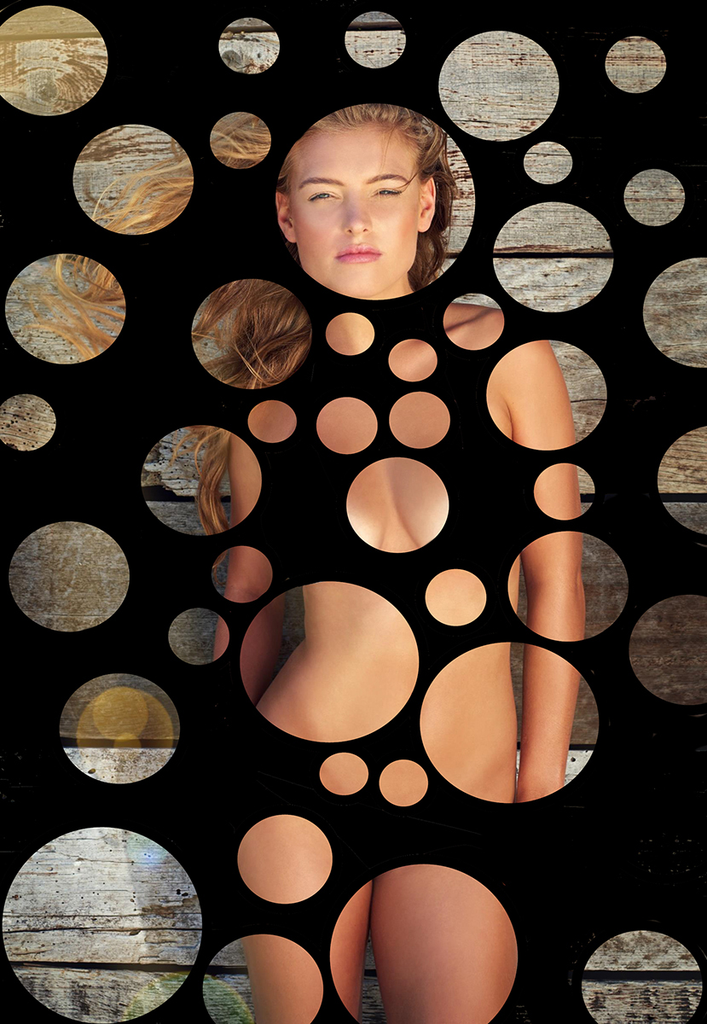

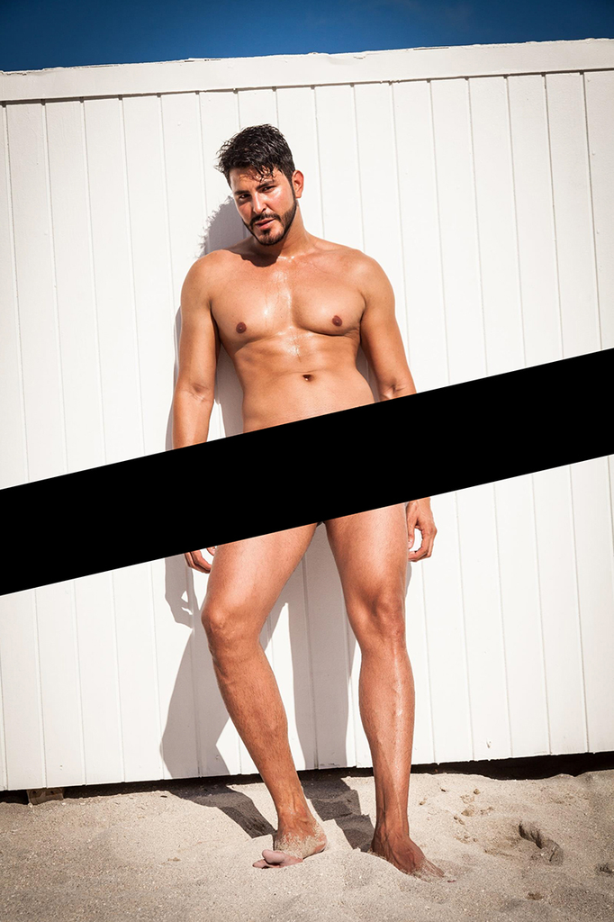

*来源*：Getty Images。

*Source*: Getty Images.

在你指责我在一本任何人都可以（也应该！）翻开的书中呈现限制级材料之前，让我再次强调，引起一些人扬起眉毛的并不是这两张图片。完全不是。这些图片没有任何异常，只是图片的某些部分恰好被涂黑了。不，引起扬眉的是*你*。是*你*走了认知捷径，才可能把图片看作限制级的例子，而不是图片本身。看起来你的心智就是不愿意把图片看正确。在这一页上，你会看到完全相同的图片，但现在没有了瑞士奶酪效果和横幅。

Before you accuse me of presenting R-rated materials in a book that could (and should!) be opened by anyone, let me reemphasize that it is not these two pictures that are the source of some raised eyebrows. Not at all. There is nothing unusual about these pictures, other than that some aspects of the pictures happen to be blackened out. No, *you* are the source of the raised eyebrows. It is *you* taking cognitive shortcuts that may perceive the picture as an R-rated example, not the picture itself. It seems your mind is simply unwilling to get the picture straight. On this page, you will see the exact same pictures but now without the Swiss cheese effect and banner.

你在这里体验到的效应，你在看日落时常常体验到，只是没有（那么）注意。当太阳落下时，它看起来可能突然被切成了两半，但我们知道，第二天早上，太阳在地平线后面依然完整而辉煌，就像穿比基尼的女士在瑞士奶酪效果后面依然完整、而那位先生在恰好挡住他泳裤的横幅后面依然完整一样。

The effect you experience here, you have often experienced without paying (as) much attention to when watching the sunset. When the sun goes down, it may seem to be suddenly cut in half, but as we know, the next morning, the sun is as complete and glorious behind the horizon as the lady in the bikini is behind the Swiss cheese effect, and the gentleman is behind the banner that happened to hide his swimsuit.

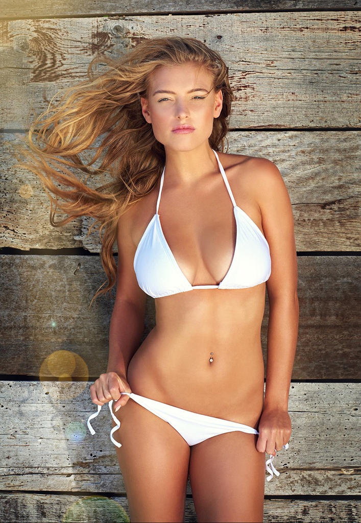

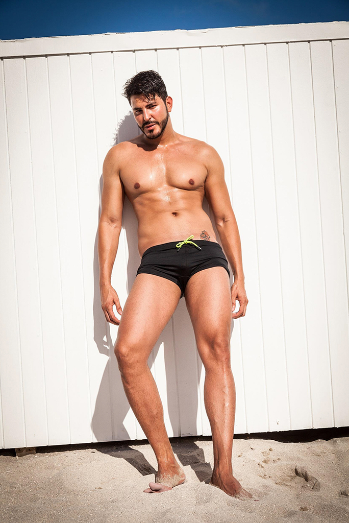

*来源*：Getty Images。

*Source*: Getty Images.

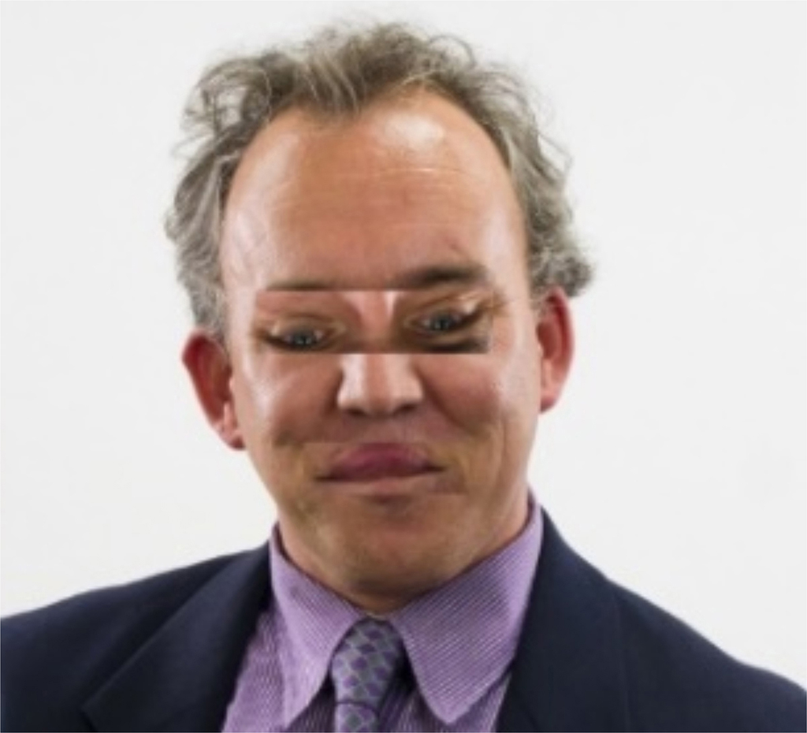

如果你的知觉模拟技能如此惊人，以至于你的心智会重演句子中呈现的信息——正如我们前面看到的那样——那么至少同样的知觉模拟技能应该能够在知觉上模拟出比基尼和泳裤，或者把一张图片转过来并注意到面部特征。但这些知觉模拟技能让你失望了。任何人工神经网络都能以很少的计算努力轻松预测出比基尼和泳裤，并识别出无论是否倒置的图片中被颠倒的眼睛和嘴。那么为什么你的人类神经网络无法完成这个简单的任务呢？

If your perceptual simulation skills are so astonishing that your mind reenacts the information presented in a sentence, as we have seen earlier, then at the very least those same perceptual simulation skills should perceptually simulate bikinis and swim trunks, or revert a picture and attend to facial features. But these perceptual simulation skills let you down. Any artificial neural network would have easily predicted bikinis and swim trunks, and identified reverted eyes and mouth in a picture upside down or not, with very little computational effort. So why has your human neural network not been able to complete this simple task?

猴子和黑猩猩也不太擅长识别倒置的图片，这一事实也许只能给你一点点安慰。当呈现黑猩猩的图像——其中一些眼睛和嘴被倒置了180度——时，黑猩猩参与者要选出与一张样本黑猩猩脸相匹配或不匹配的倒置脸。尽管它们清楚地注意到脸是否倒置的区别，但它们无法区分黑猩猩的脸是否有倒置的眼睛和嘴<sup>3</sup>——就像人类无法区分人脸一样。它们也走了认知捷径。

You might only get a little comfort out of the fact that monkeys and chimpanzees are not very good at recognizing inverted pictures either. When images of chimps were presented, some with the eyes and mouth inverted 180 degrees, the chimpanzee participants selected inverted faces that matched or did not match a sample chimp face. Even though they clearly noticed the difference between the face being upside down or not, they could not distinguish whether the chimp face had inverted eyes and mouth<sup>3</sup>—just like the humans could not for the human faces. They too had taken cognitive shortcuts.

无论你接受多少训练，无论你多么依赖你不走捷径的本能，无论你的神经网络运作得多好，也无论你激活了多少知觉模拟，你的认知懒惰都会占上风，这令人惊讶。既然这些解释是对语言加工的解释，为什么它们对图片这样简单的东西就不起作用呢？

No matter how much training you get, no matter how much you rely on your nonshortcut instincts, no matter how well your neural network functions, and no matter how many perceptual simulations you activate, your cognitive laziness prevails, which is surprising. Because these explanations are the explanations for language processing, why would they not work for something as straightforward as pictures?

“好吧，也许有些认知懒惰，但也没那么糟，”你可能会争辩说。这只是一个同时在心中保持多个视觉表征的问题，这使得处理这些例子很困难。在心中保持一张颠倒的图片，同时还要考虑被颠倒的面部特征，是很难的。在心中保持一张图片（尤其是这张图片）有或没有瑞士奶酪效果、有或没有横幅的两个版本，在认知上也相当费力。的确，我到目前为止举的例子在认知上都很费力。但语言加工也是如此。把那六万个词记在心里，获取它们的音系、形态、句法、语义和语用，同时对接下来的词作出预测，在认知上确实非常费力。

“Fair enough, there may be some cognitive laziness, but it is not that bad,” you may argue. It is merely a matter of keeping multiple visual representations in mind, which makes it difficult to deal with these examples. Keeping a reverted picture in mind together while also taking into account the facial features that are reverted is difficult. And keeping two versions of a picture (particularly this picture) with or without a Swiss cheese effect and without or without a banner in mind is also cognitively quite taxing. Indeed, the examples I have given so far are cognitively taxing. But so is language processing. Keeping those sixty thousand words in mind, and accessing their phonology, morphology, syntax, semantics, and pragmatics while making predictions about the words to come, is cognitively very taxing indeed.

### *懒惰的从众*

### *Lazy Conformity*

想象一下，你周围的人每人都拿到一张卡片，上面画着一条两英寸长的线。然后卡片被拿走，包括你在内的每个人都被问到，另一张卡片上的哪条线——一英寸、两英寸还是三英寸的线——与原来卡片上画的线最相似。对你来说这是显而易见的。当然是两英寸长的那条线，那条线看起来最像原来的线。但你小组中的七位成员并不认同。事实上，他们都一致认为不是两英寸的线，而是三英寸的线。如果你像大多数人一样，你会愿意调整你真正认为正确的东西。

Imagine the people around you are each presented with a card with a two-inch line drawn on it. The card is then taken away, and everybody, including you, is asked which of the lines on a different card are most similar to the line drawn on the original one, a line of one, two, or three inches. To you it is obvious. Of course the line that is two inches long, that one looks most like the original line. But the seven members of your group are not convinced. In fact, they all agree that it is not the two-inch line, but the three-inch line. If you are like most people, you are willing to adjust to what you really think is true.

在20世纪50年代，所罗门·阿希进行了这样的实验。<sup>4</sup>八个人围坐在一张桌子旁，看着画有不同长度线条的卡片。然而，这八个人并不都是参与者。只有一个是。其他人都被实验者仔细指示过，有时给出所有人都会同意的答案。但在另一些试次中，会出现明显的分歧。真正的参与者并没有为自己认为正确的东西而争辩，而是至少在某些情况下随大流。在事后访谈中，参与者解释说他们知道别人错了，但还是顺从了多数人。从认知上说，相当懒惰。<sup>5</sup>

In the 1950s, Solomon Asch conducted experiments like this.<sup>4</sup> Eight people were seated around a table and were presented with the cards with lines of different length. However, the eight people were not all participants. Only one was. The others were carefully instructed by the experimenter to sometimes give the answer everybody would agree on. But in some of the other trials, there would be a clear discrepancy. Rather than fighting for what the actual participant thought was right, she went along with the crowd at least in some of the cases. In a post-interview, participants explained they knew the others were wrong, but just conformed to the majority. Pretty lazy, cognitively speaking.<sup>5</sup>

回想一下我在第3章（“猜测”）中提到的那些实验。在这些实验中，阅读时记录眼睛注视，但在参与者阅读文本时，所显示的文本会被调整。也就是说，当他们注视一个词时，文本中所有其他词的字母都被替换成了*x*。如果注视点左侧四个字母位以外、右侧十五个字母位以外的字符被*x*掉，参与者的阅读过程丝毫不受妨碍。换句话说，只要划掉的部分随着他们对词的注视而移动，参与者不会注意到本书中单独一行的80%被划掉了。这是一个相当令人震惊的结论。你以为你看到了这一页上的字母，但如果有人在你阅读时神奇地划掉这些字符，你根本不会知道！当你从这一页上读这些词时，你以为你能看到你正在读的词的左边、右边、上面和下面是什么，但你看不到。你以为你看到了面前的一页，但你不能确定。<sup>6</sup>

Recall the experiments I mentioned in chapter 3 (“Guess”). In these experiments, eye gaze was recorded during reading, but the text being displayed was adjusted while participants were reading a text. That is, when they fixed on one word, the letters of all the other words in the text were replaced by *x*’s. If the characters four letter spaces to the left of the word and fifteen letters to the right of the fixation were *x*-ed out, participants were not at all hampered in their reading process. In other words, participants would not notice if 80 percent of a single line in this book were crossed out, as long as the crossing out moved with their fixations on a word. That is a rather shocking conclusion. You think you see letters on this page, but if somebody magically were to cross out the characters while you were reading, you would have no idea! While you are reading these words from the page, you think you can see what is just left, right, above, and beneath the word you read, but you don’t. You think you are seeing a page in front of you, but you cannot be certain.<sup>6</sup>

更糟的是，如果你仔细想想，我们会作出大量捷径式的假设。例如，你在阅读时假设你身后的环境仍然在那里，但这只能是一个假设（现在别回头看！）。也许某个摄制组刚刚把你身后的环境搬走了，换成了完全不同的东西。你不会知道的，除非你从认知懒人椅上站起来四处看看（而即使那样，我们刚刚也看到你不能依赖自己的感官）。所以我们假设我们看不到的东西，而如果我们能看到它们，我们的心智也已经走了捷径得出假设。

To make matters worse, if you think about it, we just make a lot of shortcut assumptions. For instance, while you are reading, you assume that the environment just behind you is still there, but this can only be an assumption (don’t look over your shoulder now!). Perhaps some film crew just removed the environment behind you and replaced this with something completely different. You would not know, unless you got out of your cognitively lazy chair and looked around (and even then we have just seen you cannot rely on your senses). So we assume things we cannot see, and if we can see them, our mind has taken shortcuts to the assumption.

这对我们迄今为止得出的结论也是令人震惊的。任何人工神经网络都能轻松识别文本中的*x*，无论它们是否以阅读速度移动，但人类神经网络却做不到。知觉模拟本应能帮助我们，但它们没有。而且即使经过训练，我们也宁愿走捷径。

This is also shocking for the conclusions we have drawn so far. Any artificial neural network would easily be able to identify *x*’s in a text, whether or not they are moving with reading speed, but a human neural network is unable to do so. Perceptual simulations should have been able to help us out, but they don’t. And even with training, we’d rather take the shortcut.

如果在并不真正知道的情况下对我们周围的世界作出假设，开始让人觉得像是《阴阳魔界》的又一集，那么我很遗憾地告诉你，这完全不是科幻。在一系列实验中，心理学家丹尼尔·西蒙斯展示了我们在变化盲视——没有看到事后看来如此明显的变化——方面走捷径的能力。你可能知道那个例子：当你在数一队篮球运动员传了多少次球时，一只大猩猩在屏幕后面跳舞。在另一项实验中，西蒙斯让一名同谋者站在柜台后面。一名作为参与者的顾客走到柜台前要取一个包裹。同谋者蹲下去拿包裹，但另一名同谋者站了起来，继续这场对话。绝大多数顾客参与者完全不知道站在他们面前的已经换了一个人。<sup>7</sup>对他们来说，走一些方便的认知捷径似乎更容易。

If making assumptions about the world around us without really knowing starts to feel like another episode of the *Twilight Zone*, I am sorry to tell you that this is not at all science fiction. In a series of experiments, psychologist Daniel Simons has shown our ability to make shortcuts when it comes to change blindness—not seeing a change that is so obvious in hindsight. You may know the example from a gorilla dancing in the back of a screen, while you are counting how many passes a team of basketball players makes. In another experiment, Simons asked a confederate to stand behind a counter. A customer participant approached the counter and asked for a package. The confederate kneeled down to pick up the package, but another confederate stood up and continued the conversation. The far majority of the customer participants had no clue somebody else was standing in front of them.<sup>7</sup> For them, making some convenient cognitive shortcuts seemed easier.

## 记忆

## MEMORY

我们不仅在知觉任务上表现不佳，在记忆任务上也表现不佳。也许更糟的是，黑猩猩在记忆任务上胜过我们。说到记忆，我们会走捷径。例如，在记电话号码时——尽管由于所有号码都安全地存在智能手机里，我在这方面越来越差了——我们会使用记忆捷径，把一长串数字组块成较小的组块，从而把这些号码记在心里。<sup>8</sup>例如，如果我们试图记住号码3 1 3 4 6 6 3 8 5 2，我们会走捷径，把这个序列组块为3 1 3—4 6 6—3 8—5 2。这节省了认知资源。

Not only do we not excel on perception tasks, but we also do not excel on memory tasks either. Perhaps even worse, chimps outperform us on memory tasks. When it comes to memory, we take shortcuts. For instance, when remembering phone numbers—though I have been getting worse at it with all the numbers safely stored in my smartphone—we use memory shortcuts to keep those numbers in mind by chunking a large sequence of numbers into smaller chunks.<sup>8</sup> For instance, if we try to remember the number 3 1 3 4 6 6 3 8 5 2, we take the shortcut of chunking the sequence into 3 1 3—4 6 6—3 8—5 2. It saves cognitive resources.

现在想象下面这个任务。我在电脑显示器上向你呈现九个数字1、2、3、4、5、6、7、8和9，如下方左图所示。你的任务是用食指按升序尽快按下每个数字。但你有时间压力。在触摸屏上按下1之后，你必须按数字2，然后同样快地按数字3。

Now imagine the following task. On a computer monitor I present you nine numbers, 1, 2, 3, 4, 5, 6, 7, 8, and 9, as presented in the picture on the left, below. Your task is to press with your index finger on each number in ascending order, as quickly as possible. But you are pressured for time. After pressing 1 on the touch screen, you will have to press the number 2, and then equally fast number 3.

现在让我们重复这个任务，但让事情复杂一点。在你按下数字1之后，在650毫秒内，所有其他数字保持位置不变，但被遮住了，如下方右图所示。不过，你仍然在做同样的任务，按升序按下数字，而且要和之前一样快。毫无疑问，你会在最初几个数字之后失败。我肯定会。

Now let’s repeat that task, but let’s make things a little more complex. After you press the number 1, within 650 milliseconds all the other numbers maintain their position, but are masked, as in the picture on the right, below. You are, however, still involved in the same task, pressing the numbers in their ascending order, and doing this as fast as you did this before. Undoubtedly, you will fail after the first numbers. I certainly do.

如果你觉得650毫秒用来记住屏幕上九个数字的位置太长了，那我们试试那个时间的三分之一，210毫秒，大约是你读这个句子中每个词（以及你迄今读过的所有其他词）所用的时间。我们把项目数从九个减到只有五个，但你只有210毫秒来扫视屏幕并储存这五个数字，然后再回忆它们的顺序。我充其量也许能记住两个数字。

If you feel that 650 milliseconds is way too much time to remember the position of the nine numbers on the screen, let’s try a third of that time, 210 milliseconds, about the time you are reading each word in this sentence (and all the others you have read so far). We will reduce the number of items from nine to only five, but you only have 210 milliseconds to glance over the screen and store the five numbers before recalling their order. I wouldn’t come further than perhaps two numbers at best.

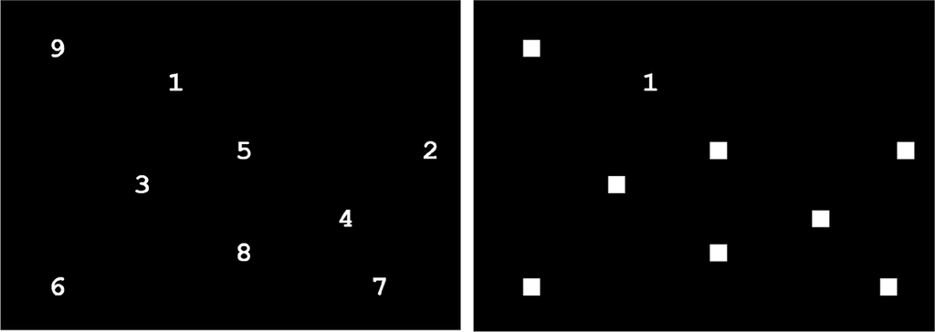

*来源*：Kawai 与 Matsuzawa（2000）。

*Source*: Kawai and Matsuzawa (2000).

现在来看看步（Ayumu），一只在京都大学接受过这项任务训练的黑猩猩。<sup>9</sup>当数字闪现650毫秒时，步回忆数字顺序的正确率为80%，实际上与人类的表现相似。但当数字显示210毫秒时，人类的表现下降到不足40%。步的表现却没有下降。它保持在80%。黑猩猩步在这项记忆任务上，无论在准确性还是速度上都击败了人类大学生。而且不是以微弱的优势。

Now let’s take Ayumu, a chimp trained on this task at Kyoto University.<sup>9</sup> Ayumu got 80 percent correct when recalling the order of numerals when they were flashed for 650 milliseconds, similar actually to human performance. But human performance decreased to less than 40 percent when the numbers were shown for 210 milliseconds. Ayumu’s performance didn’t. It stayed at 80 percent. Ayumu the chimp beat human college students on this memory task both in accuracy and in speed. And not by a small margin.

人类的表现之所以这么差，是因为认知无能还是因为认知捷径，我不知道。但鉴于到目前为止讨论的关于我们如何把那些词记在心里的解释，黑猩猩在这项任务上胜过我们这一发现至少是引人注目的。诚然，黑猩猩每完成一次任务就得到一颗花生，但无论提供多少训练，无论给予多少花生以外的奖励和正强化，你都不太可能击败步。无论我们在这项任务上投入多少脑力，我们的神经网络训练得多好，或者我们作出多少知觉模拟，黑猩猩都会击败我们。<sup>10</sup>

Whether human performance is so bad because of cognitive inability or cognitive shortcuts, I do not know. But the finding of chimps outperforming us on this task is at least remarkable given the explanations discussed so far on how we keep those words in mind. Granted, the chimps received a peanut for any successful task, but no matter how much training is provided, no matter how many rewards and how much positive reinforcement other than peanuts are given, it is unlikely you will be able to beat Ayumu. No matter how much brainpower we put into the task, how well our neural network is trained, or how many perceptual simulations we make, chimps beat us.<sup>10</sup>

你的记忆不仅对新信息不可靠。对于你非常熟悉的信息，你同样吃力。你应该相当熟悉一美元纸币。流通中的一美元纸币约有117亿张，每张一美元纸币的寿命约为5.8年。据估计，每一张印出来的美元纸币每周至少用于两次支付，所以你应该已经一遍又一遍地见过它们很多很多次了。那么让我问你，一美元纸币上的总统是谁？美国总统的脸朝左还是朝右？美国财政部的印章是在纸币的左边还是右边？你在纸币上能看到数字1几次？一次、两次、三次，也许甚至四次？哪怕有一丝犹豫，都构成了你认知懒惰的证据。如此熟悉的东西，你却无法立即认出来。

Your memory is fallible not just to new information. When it comes to information you are very familiar with, you struggle as much. You should be quite familiar with a one-dollar bill. There are some 11.7 billion dollar bills in circulation, with each one-dollar bill lasting about 5.8 years. It is estimated that each dollar bill that is ever printed is used for at least two payments a week, so you should have seen them many, many times over and over again. So let me ask you, who is the president featured on the one-dollar bill? Does the face of the president of the United States look to the left or the right? And is the U.S. treasury seal placed on the left or the right of the bill? How many times do you see the number 1 on the bill? Once, twice, trice, perhaps even four times? Even some hesitation constitutes evidence for your cognitive laziness. Something that is so familiar, you are unable to recognize instantly.

我们不仅在回忆很久以前储存的信息时走认知捷径，在依赖即时记忆时也走捷径。把手放在57°–59°F（14°–15°C）的水里，比如说一分钟，并不舒服。在一项实验中，<sup>11</sup>参与者被要求把手放在57°F/14°C的水里一分钟。在第二个试次中，参与者把另一只手放在57°F/14°C的水里六十秒，但被要求在水下再多放三十秒，在这期间水温升到了59°F/15°C。然后，参与者被要求选择他们不介意重复哪一个试次。你会预期答案是完全显而易见的。当然，如果你可以在经受一个持续六十秒的不愉快情境和一个持续九十秒的不愉快情境之间作出选择，你会毫不犹豫地选择六十秒的那个。但参与者记得自己对九十秒试次的厌恶程度低于六十秒的试次，因为至少水温稍微高了一点——但只是最后三十秒，而记住这一点显然对参与者来说需要太多认知努力了。

Not only are we taking cognitive shortcuts when remembering information we have stored from a while back, but we also take shortcuts when relying on immediate memories. Putting your hand in water of 57°–59°F (14°–15°C) for, say, one minute is not pleasant. In one experiment,<sup>11</sup> participants were asked to put their hand in 57°F/14°C water for one minute. In the second trial, participants put their other hand in 57°F/14°C water for sixty seconds, but were asked to keep it underwater for an additional thirty seconds, during which the temperature raised to 59°F/15°C. Participants were then asked to choose which trial they would not mind repeating. You would expect the answer to be totally obvious. Of course, if you can choose between being exposed to an unpleasant situation for sixty seconds and one lasting ninety seconds, you would choose the sixty-second option in a heartbeat. But participants remembered disliking the ninety-second trial less than the sixty-second one, because at least the temperature was slightly higher—but only for the last thirty seconds, which participants apparently took too much cognitive effort to remember.

所以也许你对数字序列或疼痛经历的记忆并不出色，但毫无疑问你对地理位置的记忆是无可挑剔的。让我们来检验一下你的地理知识。我假设你知道美国和加拿大一些较大地方的位置，比如旧金山、西雅图、温哥华或蒙特利尔。华盛顿特区和芝加哥，哪个更靠北？似乎不太难回答。显然芝加哥更靠北，尽管纬度只相差大约200英里。再来一个。哪个更靠北，位于加拿大安大略湖畔的多伦多，还是在温哥华以南约2.5小时车程的西雅图？这似乎同样是个简单的问题。加拿大在美国北边，所以多伦多在纬度上位于西雅图以北。但这一次你错了。在我们所有的认知懒惰中，我们假设加拿大和美国之间的边界是一条直线，但它不是。事实上，它是弯曲的，弯曲得如此厉害，以至于明尼阿波利斯和西雅图都位于多伦多以北。

So perhaps your memory is not outstanding on number sequences or pain experiences, but undoubtedly your memory for geographical locations is impeccable. Let’s check your geographical knowledge. I am going to assume that you know the location of some of the larger places in the United States and Canada, places like San Francisco, Seattle, Vancouver, or Montreal. What lies further north, Washington, DC, or Chicago? Not too difficult to answer, it seems. Obviously, Chicago lies further north, although only some 200 miles latitude difference. Here is another one. What lies further north, Toronto at Lake Ontario in Canada or Seattle, some 2.5 hours south of Vancouver? That seems to be an equally easy question. Canada lies north of the United States, so Toronto lies north of Seattle latitudinally. But here you are wrong. In all of our cognitive laziness, we assume that the border between Canada and the United States is a straight line, but it is not. In fact, it curves, so much so that Minneapolis and Seattle lie north of Toronto.

这里有一个机会来弥补这个刁钻的问题。哪个更靠西，在旧金山西北约3.5小时车程的里诺，还是就在洛杉矶以西、俯瞰太平洋的长滩？也不太难。你可能会争辩说你的纬度估计有点偏差，而这确实是一个在经度上挽回颜面的机会。但你又错了。在你所有的认知懒惰中，你很可能把长滩放在了里诺的西边。毕竟，内陆的东西在西海岸海岸线东边。但就像美国的北部边界一样，西部边界也不是直的。如果考虑经度，里诺确实位于长滩以西，也位于洛杉矶以西。<sup>12</sup>

Here is an opportunity to compensate for this trick question. What lies further west, Reno, some 3.5 hours northwest of San Francisco, or Long Beach, just west of Los Angeles, overlooking the Pacific Ocean. Not too difficult either. You may have argued that your latitude estimates were a bit off, and indeed, this is the opportunity to redeem yourself longitudinally. But you are wrong again. In all of your cognitive laziness, you likely placed Long Beach west of Reno. After all, something land-inward is east of something at the west coast ocean line. But as with the northern border of the United States, the western border is not straight. Reno really lies west of Long Beach, and west of Los Angeles if one considers their longitudes.<sup>12</sup>

不正确的估计并不止于地理位置。我们对城市人口规模的估计也表现出认知懒惰的种种迹象。美国最大的城市？纽约。你答对了。纽约市大约有900万人。那么，美洲最大的城市是哪个？纽约？错了。也许是墨西哥城？你说得对，墨西哥城比纽约大，但只多大约五十万人。答案是巴西的圣保罗，有1200万人。好吧，估计数字很难。我们来作比较。哪个更大：纽约还是土耳其的伊斯坦布尔？大苹果？错了！伊斯坦布尔比纽约多500万人。那来个简单的：巴基斯坦的卡拉奇还是纽约？嗯，这很简单，因为卡拉奇的人口是纽约的两倍。事实上，世界上最大的城市的人口几乎是纽约的三倍！

Incorrect estimates don’t stop at geographical locations. Our estimates of city population sizes also show all the signs of cognitive laziness. Largest city in the United States? New York. You got that right. Some 9 million people in New York City. Now, what is the largest city in the Americas? New York? Wrong. Mexico City perhaps? You are right that Mexico City is larger than New York, but only by some half million people. The answer is Sao Paolo in Brazil with 12 million people. Okay, estimating numbers is tough. Let’s make comparisons. Which is larger: New York or Istanbul, Turkey? The Big Apple? Wrong! Istanbul, with 5 million people more than New York. An easy one then: Karachi, Pakistan, or New York? Well, it is easy because Karachi has double the population of New York. In fact, the largest city in the world has a population almost three times higher than New York!

说到估计，我们一直都在出错。让我用一系列问题及其答案来说明，这些问题取自达菲2018年的《感知的危险》（*Perils of Perception*），我们来比较一下数字。下面你会看到一些问题。读问题时，试着先自己想出一个答案，然后再看右边。右边的数字显示的是你的同胞们所作的平均猜测，后面是现实中的实际数字。你的估计很可能与你同胞们的估计非常相似，而与右边的数字相比，错得非常离谱。

When it comes to estimates, we are off all the time. Let me illustrate with a range of questions and their answers, taken from Duffy’s 2018 *Perils of Perception*, and let’s compare the numbers. Below you will find some questions. When you read the question, try to come up with an answer yourself, and only then look to the right. The numbers on the right show the average guesses your fellow countrymen make, followed by the actual numbers in reality. Your estimates are likely very similar to those of your fellow countrymen, and when compared to the number to the right, very wrong.

[output not shown]

*来源*：Duffy（2018）。

*Source*: Duffy (2018).

如你所见，别人所猜的与实际之间的差异很大，多达20–40%！我打赌你同胞们的估计与你自己的估计非常一致。我们不依赖事实；我们宁愿依赖我们悲观的认知捷径。

As you can see, the differences between what others had guessed and the actual difference is large, as much as 20–40 percent! I bet the estimates from your fellow countrymen were very much in line with your own estimates. We don’t rely on the facts; we’d rather rely on our pessimistic cognitive shortcuts.

甚至不只是对已知信息，你的记忆也会让你失望。对于你试图记住的新信息也是如此。例如，看看下面这个词表，试着把它们记在心里。

And it is not even with known information that your memory lets you down. The same can be said for new information you try to remember. For instance, have a look at the following list of words, and try to keep them in mind.

| sour（酸） sour | candy（糖果） candy | sugar（糖） sugar | bitter（苦） bitter | good（好） good | taste（味道） taste | tooth（牙齿） tooth | nice（美好） nice |
| --- | --- | --- | --- | --- | --- | --- | --- |
| honey（蜂蜜） honey | soda（汽水） soda | chocolate（巧克力） chocolate | heart（心） heart | cake（蛋糕） cake | tart（馅饼） tart | pie（派） pie |  |

现在把这本书放到一边，写下（或想一想）你能回忆起来的所有项目。这其实是20世纪90年代中期的一项实验。<sup>13</sup>参与者被要求记住一个像这样的词表，然后接受一个再认测试。没什么挑战性，因为你记住了这些词，你所需要做的只是列出你认出的词：*elephant*（大象）、*mouth*（嘴）、*candy*（糖果）、*honey*（蜂蜜）、*tooth*（牙齿）、*sweet*（甜）、*pie*（派）。毫无疑问，你否认见过*elephant*，对*mouth*犹豫了一下，并认出其他所有词都是词表的一部分。而你错了。尽管所有项目都与甜有关，*sweet*这个词从未出现在词表中。你的记忆产生了虚假的回忆。你以为你看到了你从未看到过的东西。

Now put this book away and write down (or think of) all the items you can recall. This was actually an experiment in the mid-1990s.<sup>13</sup> Participants were asked to remember a word list like this and were then exposed to a recognition test. Nothing challenging, as you remembered the words, and all you need to do is list which words you recognize: *elephant, mouth, candy, honey, tooth, sweet, pie*. Undoubtedly, you rejected having seen *elephant*, hesitated on *mouth*, and recognized all the others as being part of the list. And you were wrong. Even though all items are related to sweetness, the word *sweet* never appeared in the list. Your memory produced false recollections. You thought you had seen something that you had never seen.

## 认知

## COGNITION

我们现在已经看到了许多来自知觉和记忆的例子，展示了我们的认知懒惰。还有许多这样的例子痛苦地提醒我们，我们在思考上有多懒惰。事实上，在许多方面，我们的认知技能并不胜过我们的灵长类同伴——黑猩猩。

We have now seen a number of examples from perception and memory demonstrating our cognitive laziness. There are many more of these examples that painfully remind us how lazy we are in our thinking. In fact, in many respects our cognitive skills do not beat those of our fellow primates, the chimpanzees.

这似乎很简单。人类的相对脑容量是同等体型灵长类的三倍。人类的大脑皮层比其他灵长类更发达。因此，这些更大的大脑使我们人类能够比其他物种更好地完成各种认知任务——更强的记忆、更快的学习、更快的知觉加工、更可靠的推理、更好的计划、更好的符号加工——也就不足为奇了。一组来自德国、西班牙和美国的研究者通过比较一系列任务与我们最近的祖先黑猩猩的表现，检验了这是否属实。<sup>14</sup>他们得出了一个与你开始读这一章之前似乎显而易见的结论不同的结论。他们要求人类儿童和黑猩猩完成一系列任务，从找到奖励到用一根棍子取回够不着的奖励。在许多认知任务上，人类——至少是德国的105名约2.5岁的人类儿童——并不比黑猩猩——至少是生活在乌干达或刚果共和国的106只黑猩猩——做得更好。在找到奖励、在奖励被旋转后追踪它、以及区分数量和数字相加方面，黑猩猩做得和人类一样好。

It seems so simple. Humans have a relative brain size three times bigger than primates of the same body size. Humans have a cerebral cortex that is more developed than that of other primates. And it would therefore be no surprise that these bigger brains allow us humans to perform all kinds of cognitive tasks better than other species: greater memory, faster learning, faster perceptual processing, more robust inferences, better planning, better symbolic processing. A group of researchers from Germany, Spain, and the United States tested whether this is true, by comparing a battery of tasks to our closest ancestor, the chimpanzee.<sup>14</sup> And they came to a different conclusion than what seemed to be obvious before you started reading this chapter. They asked human children and chimpanzees to perform a number of tasks, ranging from locating a reward to using a stick in order to retrieve a reward that was out of reach. On many cognitive tasks, humans, at least 105 human children in Germany of about 2.5 years of age, did not do better than chimpanzees, at least 106 chimpanzees that lived in Uganda or the Republic of Congo. On locating a reward, on tracking the reward after it got rotated, and on discriminating quantities and adding numbers, the chimps did as well as the humans.

你可能会争辩说，一个2.5岁孩子的认知表现与同龄黑猩猩不相上下，但随着年龄增长，我们会迅速成长为具有更优越的认知表现。这是对的，但我们的认知才华常常出错。或者更确切地说，我们宁愿走认知捷径而不是讲逻辑，正如阿莫斯·特沃斯基和丹尼尔·卡尼曼在一系列实验中所表明的那样。也许最著名的实验是银行出纳员琳达的实验。三组人参加了这项研究：一组对统计学、概率论和决策理论一无所知的本科生；一组有一定了解的心理学、教育学和医学专业的一年级研究生；以及一组在统计学、概率论和决策理论方面受过高级训练的决策科学博士候选人。三组参与者都看到了以下文字：

You may argue that the cognitive performance of a 2.5-year-old is on par with that of a chimpanzee of a similar age, but that we rapidly grow to superior cognitive performance when we get older. That is true, but our cognitive brilliance is often off. Or rather, we’d rather go for cognitive shortcuts than for logic, as Amos Tversky and Daniel Kahneman have shown in a series of experiments. Perhaps the most famous experiment is the one with bank teller Linda. Three groups participated in the study: a group of undergraduate students naïve to statistics, probability, and decision theory; an informed group of first-year graduate students in psychology, education, and medicine; and a sophisticated group of PhD candidates in decision science with advanced studies in statistics, probability, and decision theory. All three groups of participants were presented with the following text:

> 琳达31岁，单身，直言不讳，非常聪明。她主修哲学。作为学生，她深切关注歧视和社会公正问题，还参加过反核示威。以下哪一项可能性更大？

> Linda is 31 years old, single, outspoken, and very bright. She majored in philosophy. As a student, she was deeply concerned with issues of discrimination and social justice, and also participated in anti-nuclear demonstrations. Which is more probable?
> 1. 琳达是一名银行出纳员。  
>    Linda is a bank teller.
> 2. 琳达是一名银行出纳员，并且积极参与女权运动。  
>    Linda is a bank teller and is active in the feminist movement.

天真组中约89%的参与者、了解组中90%的参与者以及精通组中85%的参与者回答了选项2。在第二个实验中重复了这一点，同样——绝大多数参与者选择了第二个选项。你会属于多数派，还是属于那10–15%的少数派？

Some 89 percent of the participants in the naïve group, 90 percent in the informed group, and 85 percent in the sophisticated group answered option 2. This was repeated in a second experiment, when—again—the vast majority of the participants opted for the second option. Would you belong to the majority group or the minority of 10–15 percent of the participants?

不需要多少逻辑思维就能知道，第二个选项的可能性远小于第一个。打个比方：你是本书的读者的可能性，大于你是本书的女性读者（或男性读者）的可能性。类似地，你是银行出纳员的可能性远大于你是女权主义银行出纳员的可能性。然而，一条认知捷径很可能（大约有85%的概率）把你推向了合取谬误。

It does not take much logical thinking to know that the second option is far less likely than the first one. To make an analogy: it is more likely that you are a reader of this book, than that you are a female reader of this book (or a male reader). Similarly, it is far more likely that you are a bank teller than that you are a feminist bank teller. And yet, a cognitive shortcut likely (with some 85 percent probability) pushed you toward a conjunction fallacy.

现在你可能会反对说你对这段文字的理解不同。其实，你把它理解为有两个选项：“琳达*只*是一名银行出纳员，不是女权主义者”*或者*“她是一名银行出纳员，并且也积极参与女权运动”。人们通常并不是这样回答这类例子的，但也许你是那个不那么认知懒惰的例外。为了确定那85%的参与者也不属于这个例外，可以向他们呈现合取谬误背后的论证，基本上就是让他们面对这个错误，并问他们会选择哪个论证。<sup>15</sup>

Now you may object that you read the text differently. Really, you had read it as if you had two options: “Linda is *only* a bank teller and not a feminist” *or* that “she is a bank teller and also active in a feminist movement.” That’s not quite how people generally respond to examples like these, but perhaps you are the not-so-cognitively-lazy exception. To be certain that 85 percent of the participants do not belong to this exception either, one could present them with the arguments behind the conjunction fallacy, basically confronting them with the error and asking them which argument they would choose.<sup>15</sup>

> *论证1*

> *Argument 1*

> 琳达是银行出纳员的可能性大于她是女权主义银行出纳员的可能性，因为每个女权主义银行出纳员都是银行出纳员，但有些女银行出纳员不是女权主义者，而琳达可能就是其中之一。

> Linda is more likely to be a bank teller than she is to be a feminist bank teller, because every feminist bank teller is a bank teller, but some women bank tellers are not feminists, and Linda could be one of them.

> *论证2*

> *Argument 2*

> 琳达是女权主义银行出纳员的可能性大于她是银行出纳员的可能性，因为她更像一名积极的女权主义者，而不像一名银行出纳员。

> Linda is more likely to be a feminist bank teller than she is likely to be a bank teller, because she resembles an active feminist more than she resembles a bank teller.

面对这些论证时，答错的概率从之前的85%有所下降，但仍有65%的参与者选择了第二个选项。他们仍然不想从懒人椅上站起来。

When confronted with the argument, the probability of getting it wrong decreased from the previous 85 percent, but still 65 percent of the participants chose the second option. They still did not want to get out of their lazy chair.

但走认知捷径并不止于银行出纳员和女权运动。它延续到了鲨鱼身上。鲨鱼，你不讨厌它们吗？光是想想就够了。你正在海滩边游泳，又发生了一次鲨鱼袭击。还记得前段时间佛罗里达米拉玛海滩的那次吗？加利福尼亚圣迭戈附近海滩的另一次呢？再也没人想在海里游泳了，因为你还没反应过来，又一条大白鲨就开始啃你的脚了。那么让我问几个傻问题。哪个更有可能：你死于鲨鱼袭击，还是死于枪支意外走火？你死于鲨鱼袭击，还是死于被食物噎住？你死于鲨鱼袭击，还是死于香槟瓶塞？

But taking cognitive shortcuts does not stop with bank tellers and feminist movements. It continues with sharks. Sharks, don’t you hate them? Just the thought of it. You are swimming along the beach, and there is yet another shark attack. Remember that one at Miramar Beach in Florida a while back? The other one at the beach close to San Diego in California? Nobody wants to swim in the ocean anymore, because before you know it another Great White has started nibbling at your feet. So let me raise some silly questions. What is more likely: that you die from a shark attack or from an accidental gun discharge? That you die from a shark attack or choking on food? That you die from a shark attack or a champagne cork?

| **死因** **Cause of Death** | **死亡概率** **Odds of Dying** |
| --- | --- |
| 心脏病 Heart Disease | 1 in 6 |
| 癌症 Cancer | 1 in 7 |
| 慢性下呼吸道疾病 Chronic Lower Respiratory Disease | 1 in 27 |
| 自杀 Suicide | 1 in 88 |
| 阿片类药物过量 Opioid overdose | 1 in 96 |
| 机动车事故 Motor Vehicle Crash | 1 in 103 |
| 跌倒 Fall | 1 in 114 |
| 枪击 Gun Assault | 1 in 285 |
| 行人事故 Pedestrian Incident | 1 in 556 |
| 摩托车手 Motorcyclist | 1 in 858 |
| 溺水 Drowning | 1 in 1,117 |
| 火灾或烟雾 Fire or Smoke | 1 in 1,474 |
| 被食物噎住 Choking on Food | 1 in 2,696 |
| 骑自行车者 Bicyclist | 1 in 4,047 |
| 枪支意外走火 Accidental Gun Discharge | 1 in 8,527 |
| 中暑 Sunstroke | 1 in 8,912 |
| 触电、辐射、极端温度和压力 Electrocution, Radiation, Extreme Temperatures and Pressure | 1 in 15,638 |
| 锐器 Sharp objects | 1 in 28,000 |
| 灾难性风暴 Cataclysmic Storm | 1 in 31,394 |
| 高温表面和物质 Hot surfaces and substances | 1 in 46,045 |
| 大黄蜂、黄蜂和蜜蜂蜇伤 Hornet, wasp and bee stings | 1 in 46,562 |
| 被狗咬 Dog attack | 1 in 115,111 |
| 飞机乘客 Passenger on an airplane | 1 in 188,364 |
| 雷击 Lightning | 1 in 218,106 |
| 铁路乘客 Railway passenger | 1 in 243,765 |

*来源*：美国国家安全委员会根据美国国家卫生统计中心死亡率数据所作的估计。

*Source*: National Safety Council estimates based on data from National Center for Health Statistics—Mortality Data.

事实上，与其说死于鲨鱼袭击，不如说更可能死于在医院感染、过度寒冷或沙坑坍塌。而且死于香槟瓶塞的可能性要大得多。香槟瓶塞？没错：每年大约有二十几个人被香槟瓶塞打死，婚礼是最常发生这种事的场合。而每年被鲨鱼袭击致死的只有十六人。十六个也太多了，但你一生中可能从未害怕过香槟瓶塞，而现在你意识到你应该害怕。

In fact, rather than dying from a shark attack, it is far more likely to die from contracting an infection in a hospital, an excessive cold, or a sand-hole collapse. And it is far more likely to die from a champagne cork. A champagne cork? Yes, that’s right: approximately two dozen people are killed by champagne corks each year, with weddings the most common place this happens. There are only sixteen people killed by shark attacks each year. That is sixteen too many, but you probably never feared a champagne cork in your life and now realize you should.

想象一下，出于怀旧，你对普林斯的某张专辑感兴趣。你在eBay上搜索，有点出乎意料的是，有人以22.67美元出售这件物品。你需要出价。你会出多少？也许22.80美元？也许23美元？现在你已经掌握了窍门，你还在找普林斯的另一张专辑。那张也在网上，只要20.00美元。你会出多少？你很可能会出价25美元左右。这就有意思了。你的出价是由原价决定的。当然，它不应该如此。假设你认为两张专辑的价值相近（我甚至都没告诉你是哪两张专辑，所以假设它们价格相近似乎是合理的），你出不同的价不是基于它们的价值，而是基于给你的价格。而且，对于其中一张专辑，你的出价可能会以小幅递增（毕竟，小数点恰恰会促使你这样做），而对另一张专辑则以较大幅度递增（尽管原价更低）。你这是怎么了？

Imagine out of nostalgia you are interested in that one Prince album. You search on eBay, and somewhat to your surprise, somebody sells the item for $22.67. You need to place a bid. What would your bid be? Perhaps $22.80? Perhaps $23? Now you have already gotten the hang of it, and you were also looking for that other Prince album. That one too is available online, for only $20.00. What would your bid be? Most likely you would place a bid for $25 or so. Now, this is funny. Your bid is determined by the original price. Of course, it shouldn’t be. Assuming that you would value the two albums similar in price (and I have not even told you which albums they were, so it seems to be a reasonable assumption they are similar in price), you would place different bids not on their value, but on the price given to you. Moreover, your bid is likely to occur in small increments in the case of the one album (after all, the decimals trigger you to do exactly that), but in larger increments of the other album (even though the original price was lower). What has gotten into you?

基本上，你锚定了你的估计。卡尼曼和特沃斯基注意到，给人们的初始值会影响他们的估计。<sup>16</sup>例如，一组参与者被给予五秒钟来估计下面这个数学算式的结果。

Basically, you anchor your estimates. Kahneman and Tversky noted initial values given to people affected their estimates.<sup>16</sup> For instance, one group of participants were given five seconds to estimate the total of the following mathematical equation.

1 × 2 × 3 × 4 × 5 × 6 × 7 × 8

另一组看到同样的算式，但顺序相反：

Another group saw the same equation, but now in reverse:

8 × 7 × 6 × 5 × 4 × 3 × 2 × 1

第一组给出的估计大约是512，而第二组的估计高出四倍多，为2,250。实际上两组参与者都差得很远，正确结果是40,320。基本上，参与者表现出了卡尼曼和特沃斯基所说的锚定与调整启发式。在一项类似的研究中，卡尼曼和特沃斯基操纵了一个幸运轮，使它总是停在10或65上。参与者被问到：“非洲国家在联合国中所占的百分比是高于还是低于幸运轮上的数字？”接着又问：“非洲国家在联合国中占百分之多少？”

The estimate given by the first group was approximately 512, but that of the second group was over four times higher at 2,250. Now both groups of participants were well off, with the correct outcome being 40,320. Basically, participants were demonstrating what Kahneman and Tversky called anchoring and adjustment heuristic. In a similar study, Kahneman and Tversky rigged a wheel of fortune so it would always land on either 10 or 65. Participants were asked, “Was the percentage of African countries in the United Nations higher or lower than the number from the wheel of fortune?” followed by the question “What percentage of African countries are in the United Nations?”

看到数字10的参与者平均猜测为25%，而看到数字65的参与者平均猜测为45%。<sup>17</sup>要点在于，估计值因为转动了一个被操纵的幸运轮而改变了。我们的认知懒惰让我们更依赖一个被操纵的幸运轮，而不是我们的记忆。锚定与调整的观念相当强大，在印象形成中也能找到。我们喜欢在聚会上与之交谈的那个人吗？我们不喜欢他或她吗？为什么？下面你会看到一段文字摘录。我不是要你仔细阅读这段文字，而是浏览一下，比如说只花几秒钟。在1到10的量表上，你有多喜欢约翰逊小姐？

Those participants presented with the number 10 had an average guess of 25 percent, but those presented with the number 65 had an average guess of 45 percent.<sup>17</sup> The point is that the estimates changed because of the spinning of a rigged wheel of fortune. Our cognitive laziness lets us rely more on a rigged wheel of fortune than our memory. The idea of anchoring and adjustment is rather powerful, and can also be found in impression formation. Do we like the person we talk to at that party? Do we dislike him or her? And why? Below you see an excerpt from a text. I am not asking you to carefully read the text, but to skim through it, say for just a few seconds. How much do you like Miss Johnson on a scale of one to ten?

> 约翰逊小姐仪表出众，才艺过人。她标榜高尚的情操。但她的心灵贫乏，她的心天生荒芜；那片土壤上没有什么能自然地开花；没有任何不经强求的天然果实以其新鲜令人愉悦。她非常爱炫耀，但她并不真诚。她不善良；她没有独创性；她常常重复书中那些响亮的词句；她从不提出、也从不拥有自己的观点，但她不懂得同情和怜悯的感受；温柔和真诚不在她身上。她不值得嫉妒：她低劣得引不起任何感情。请原谅这看似矛盾的说法；我是认真的。

> Miss Johnson had a fine person, many brilliant attainments. She advocated a high tone of sentiment. But her mind was poor, her heart barren by nature; nothing bloomed spontaneously on that soil; no unforced natural fruit delighted by its freshness. She was very showy, but she was not genuine. She was not good; she was not original; she used to repeat sounding phrases from books; she never offered, nor had, an opinion of her own, but she did not know the sensations of sympathy and pity; tenderness and truth were not in her. She was a mark beneath jealousy: she was too inferior to excite feeling. Pardon the seeming paradox; I mean what I say.

现在请你对下面这段文字做同样的事，同样只花几秒钟浏览一下，但现在判断你有多喜欢彼得森小姐。

Now let me ask you to do the same for the following text, again spending only a few seconds skimming through it, but now determining how much you like Miss Pederson.

> 彼得森小姐不值得嫉妒：她低劣得引不起任何感情。请原谅这看似矛盾的说法；我是认真的。她非常爱炫耀，但她并不真诚；她仪表出众，才艺过人，但她的心灵贫乏，她的心天生荒芜；那片土壤上没有什么能自然地开花；没有任何不经强求的天然果实以其新鲜令人愉悦。她不善良；她没有独创性；她常常重复书中那些响亮的词句；她从不提出、也从不拥有自己的观点。她标榜高尚的情操，但她不懂得同情和怜悯的感受；温柔和真诚不在她身上。

> Miss Pederson was a mark beneath jealousy: she was too inferior to excite feeling. Pardon the seeming paradox; I mean what I say. She was very showy, but she was not genuine; she had a fine person, many brilliant attainments, but her mind was poor, her heart barren by nature; nothing bloomed spontaneously on that soil; no unforced natural fruit delighted by its freshness. She was not good; she was not original; she used to repeat sounding phrases from books; she never offered, nor had, an opinion of her own. She advocated a high tone of sentiment, but she did not know the sensations of sympathy and pity; tenderness and truth were not in her.

你觉得哪个文本人物更好，约翰逊小姐还是彼得森小姐？<sup>18</sup>很可能约翰逊小姐胜过了彼得森小姐。那就有意思了，因为两段描述是完全相同的。不过，描述的顺序不同。在第一段摘录中，先呈现正面特征；在第二段中，正面特征立即被负面特征抵消了。然而，我们的认知懒惰让我们根据第一印象来判断一个人。如果我们的第一印象好，就很难让它变坏。如果我们的第一印象坏，就很难用好的印象来弥补。我们基本上让第一印象支配所有的印象，尽管我们知道第一眼是会骗人的。我们走了一条认知捷径！

Which text character did you rate as nicer, Miss Johnson or Miss Pederson?<sup>18</sup> Most likely Miss Johnson won from Miss Pederson. That would be funny, because the descriptions are identical. The order of the descriptions differed, however. In the first excerpt, positive features were presented first, in the second, positive features were immediately countered by negative features. However, our cognitive laziness lets us determine somebody by first impressions. If our first impressions are good, then it is hard to make them bad. If our first impressions are bad, it is hard to compensate with good impressions. We basically let our first impressions govern all impressions, knowing that first looks are deceiving. We take a cognitive shortcut!

1948年，心理学教授伯特伦·福勒想知道，他能否根据学生的测试结果来描述他们的性格。他为三十九名学生中的每一个人写了一份简短的个人性格描述，并问每个学生这份性格描述在多大程度上适用于他们。这样一份描述的一个例子如下：

In 1948 psychology professor Bertram Forer wondered whether he could describe the personality of his students on the basis of their test results. For each of his thirty-nine students, he wrote a brief personal personality sketch and asked each of the students to what extent the personality sketch applied to them. One example of such a sketch looked like this:

> 你非常需要别人喜欢和欣赏你。你有自我批评的倾向。你有大量尚未利用的能力，还没有把它们转化为自己的优势。虽然你在性格上有一些弱点，但你通常能够弥补它们。你在性方面的适应曾给你带来过问题。你外表自律、自制，内心却往往忧虑不安。有时你会严重怀疑自己是否作出了正确的决定或做了正确的事。你喜欢一定程度的变化和多样性，在受到约束和限制时会感到不满。你以独立思考者自居，不会在没有令人满意的证据的情况下接受别人的说法。你发现过于坦率地向别人袒露自己是不明智的。有时你外向、和蔼、善于交际，而在另一些时候你内向、谨慎、矜持。你的一些抱负往往相当不切实际。安全感是你人生的主要目标之一。<sup>19</sup>

> You have a great need for other people to like and admire you. You have a tendency to be critical of yourself. You have a great deal of unused capacity which you have not turned to your advantage. While you have some personality weaknesses, you are generally able to compensate for them. Your sexual adjustment has presented problems for you. Disciplined and self-controlled outside, you tend to be worrisome and insecure inside. At times you have serious doubts as to whether you have made the right decision or done the right thing. You prefer a certain amount of change and variety and become dissatisfied when hemmed in by restrictions and limitations. You pride yourself as an independent thinker and do not accept others’ statements without satisfactory proof. You have found it unwise to be too frank in revealing yourself to others. At times you are extroverted, affable, sociable, while at other times you are introverted, wary, reserved. Some of your aspirations tend to be pretty unrealistic. Security is one of your major goals in life.<sup>19</sup>

每个学生都被要求在0到5的量表上评定这份描述对自己的适用程度。如果描述完全吻合，学生打5分；如果更像是不吻合，就打0分。福勒的努力得到了回报。学生们对福勒专门为他们写的描述给出了平均4.3分的准确度，只不过每个人收到的都是同一份描述！要么这三十九名学生完全一样——一个相当不可能的结论——要么学生们运用了认知捷径，找到了适用于自己的模式。尤其是在说的都是正面的话时，我们喜爱那些模式。

Each of the students was asked to rate how the sketch applied to them on a scale of zero to five. If the sketch was an absolutely perfect match, a student scored a 5; if the match was more like a mismatch, a score of 0 was given. Forer’s efforts paid off. Students gave an average accuracy of 4.3 for the sketch that Forer had made especially for them, except that everybody received the same sketch! Either all thirty-nine students were exactly the same—a rather unlikely conclusion—or the students applied cognitive shortcuts and found patterns that applied to them. And particularly with positive words being spoken, we love those patterns.

## 语言

## LANGUAGE

我们的语言技能非同寻常。在本章中，我们已经看到，我们的知觉模拟技能、我们的记忆技能以及我们的计算，并不像我们可能以为的那样令人印象深刻。有人因此可以认为，它们是否是我们成为语言天才的最佳解释是值得怀疑的。但即使考虑到我们非凡的语言技能，也有令人担忧的理由。毕竟，我们能够解析各种句法结构的复杂句子，但我们几乎不运用这种技能。尽管我们能够生成具有递归特征的复杂句子——一个句子嵌入另一个句子，后者又可能嵌入另一个句子，其从句又可以嵌入另一个句子，如此等等——我们几乎看不到这样的句子。如果我们的语言本能是对语言加工的解释，我们为什么不产出这么长的句子呢？或者为什么我们在这些句子上吃力呢？像这样的句子：

Our linguistic skills are remarkable. In this chapter, we have seen that our perceptual simulation skills, our memory skills, as well as our computations are not as impressive as we may have thought. One could argue that it is therefore questionable whether they are the best explanation for us being a language genius. But even when we consider our remarkable language skills, there is reason for concern. After all, we are able to parse complex sentences in a variety of syntactic structures, but we hardly apply this skill. Even though we are able to generate complex sentences, that have aspects of recursion—so that a sentence is embedded in another sentence, which may be embedded in another sentence, whose subordinate clause can be embedded in yet another sentence, and so forth—we hardly see these sentences. If our language instinct is an explanation of language processing, why don’t we produce such long sentences? Or why do we struggle with these sentences? Sentences like this one:

> 就跟父亲一模一样，要是父亲在我去那儿的前一天晚上就像他在我回来后的第二天那样对此了解得那么多的话，心里想着，疯狂而无能的老人，终于意识到即使是一个恶魔作恶的能力也必定有某种限度，他一定已把自己的处境看作那个歌舞女郎、那匹小马的处境，她意识到她随之腾跃的主旋律并非来自号角、提琴和鼓，而是来自钟表和日历，一定已把自己看作那门破旧不堪的老炮，它意识到自己只能再猛烈地发出一炮，然后就在自己狂暴的爆炸和后坐力中化为齑粉，他环顾仍在他视野和掌控之内的场景，看到儿子走了，消失了，如今对他来说比儿子死了还要无法逾越，因为现在（如果儿子还活着）他的名字会不一样，叫他这个名字的人会是陌生人，而儿子可能在随便哪个陌生女人身上播下的萨德本血脉的任何龙种，因此都将延续这一传统，在另一个名字之下、在那些永远不会听到正确名字的人们之上和之中，完成这世袭的邪恶与伤害。<sup>20</sup>

> Just exactly like Father if Father had known as much about it the night before I went out there as he did the day after I came back thinking Mad impotent old man who realized at last that there must be some limit even to the capabilities of a demon for doing harm, who must have seen his situation as that of the show girl, the pony, who realizes that the principal tune she prances to comes not from horn and fiddle and drum but from a clock and calendar, must have seen himself as the old wornout cannon which realizes that it can deliver just one more fierce shot and crumble to dust in its own furious blast and recoil, who looked about upon the scene which was still within his scope and compass and saw son gone, vanished, more insuperable to him now than if the son were dead since now (if the son still lived) his name would be different and those to call him by it strangers and whatever dragon’s outcropping of Sutpen blood the son might sow on the body of whatever strange woman would therefore carry on the tradition, accomplish the hereditary evil and harm under another name and upon and among people who will never have heard the right one.<sup>20</sup>

这是一个长达1288词的句子的前217个词。诚然，整个句子是文学中最长的句子，出自威廉·福克纳的《押沙龙，押沙龙！》（*Absalom! Absalom!*），但我们并不太欣赏它的长度和句法结构。我们的语言本能完全能够理解这个语法结构，但我们宁愿走捷径，因为这需要太多的认知努力，而我们是认知懒惰的。*努力*和*捷径*可不怎么相配。正如我在第3章中所表明的，我们有时会遇到花园路径句，即在我们开始读一个句子时把我们引上歧途的句子。例如下面这些句子<sup>21</sup>：

These are the first 217 words of a 1288-word sentence. Granted, the entire sentence is the longest sentence in literature, from William Faulkner’s *Absalom! Absalom!*, but we do not quite appreciate its length and syntactic structure. Our language instinct is perfectly able to understand the grammatical structure, but we’d rather go for the shortcut, as it takes too much cognitive effort and we are cognitively lazy. And *effort* and *shortcut* do not go together well. As I showed in chapter 3, we sometimes experience garden-path sentences, sentences that lead us astray on the syntactic path we chose when starting out the sentence. Sentences such as the following<sup>21</sup>:

- The complex houses married and single soldiers and their families.（这片建筑群为已婚和单身士兵及其家属提供住所。）  
  The complex houses married and single soldiers and their families.
- Sam ate the hot dog and the vegetables went untouched.（萨姆吃了热狗，蔬菜一口没动。）  
  Sam ate the hot dog and the vegetables went untouched.
- The government plans to raise taxes were defeated.（政府提高税收的计划被否决了。）  
  The government plans to raise taxes were defeated.
- The investigation revealed the error resulted from gross negligence.（调查表明，这一错误是由严重疏忽造成的。）  
  The investigation revealed the error resulted from gross negligence.

这些都是完全合乎语法的句子，但我们会在上面绊倒。我们精力充沛的语言本能本应毫无困难——确实，我们能够解析它们——但我们噎住了。我们重读，再试一次，直到找到一个行得通的句法结构。正如我们在第3章中看到的，这些花园路径句让你走上一条句法结构之路，当你意识到自己卡住了，就需要选择另一条路。我们认知懒惰的证据在于，花园路径句在测试它们的研究实验室之外并不经常出现。你有多少次在一个句子的语法结构上绊倒过？这几乎从未发生过，因为作者或说话者已经为你提供了足够的语境，让你作出正确的预测和正确的认知捷径。当花园路径句确实出现时，比如在报纸标题中，它们常常导致相当滑稽的解读：

These are perfectly grammatical sentences, but we stumble over them. Our energetic language instinct should have no difficulty with them—and indeed, we are able to parse them—but we choke. We reread, and try again, until we have found a syntactic structure that works. As we have seen in chapter 3, these garden-path sentences get you to walk on one syntactic structure path, and when you realize you are stuck, you need to decide on another path. The evidence of our cognitive laziness is the fact that garden-path sentences do not occur very frequently outside the research labs in which they are tested. How often have you tripped over the grammatical structure of a sentence? It hardly ever happens, because the writer or speaker has provided you with enough context to make the right predictions and the right cognitive shortcut. When garden-path sentences do occur, as in newspaper headlines, they often lead to rather humorous interpretations:

- Chinese Cooking Fat Heads for Holland（中国食用油运往荷兰／中国厨师胖头前往荷兰）  
  Chinese Cooking Fat Heads for Holland
- Miners Refuse to Work after Death（矿难后矿工拒绝工作／矿工拒绝死后工作）  
  Miners Refuse to Work after Death
- Dr. Ruth to Talk about Sex with Newspaper Editors（露丝博士将与报纸编辑谈论性话题／露丝博士将谈论与报纸编辑发生性关系）  
  Dr. Ruth to Talk about Sex with Newspaper Editors
- Lung Cancer in Women Mushrooms（女性肺癌激增／女性蘑菇中的肺癌）  
  Lung Cancer in Women Mushrooms
- Teacher Strikes Idle Kids（教师罢工使孩子们无所事事／教师殴打懒散的孩子）  
  Teacher Strikes Idle Kids
- Enraged Cow Injures Farmer with Axe（发怒的牛伤了拿斧头的农夫／发怒的牛用斧头伤了农夫）  
  Enraged Cow Injures Farmer with Axe
- Squad Helps Dog Bite Victim（小队帮助被狗咬的受害者／小队帮狗咬受害者）  
  Squad Helps Dog Bite Victim
- Juvenile Court Tries Shooting Defendant（少年法庭审理枪击案被告／少年法庭试图枪击被告）  
  Juvenile Court Tries Shooting Defendant
- Killer Sentenced to Die for Second Time in 10 Years（杀手十年内第二次被判死刑／杀手被判十年内第二次死去）  
  Killer Sentenced to Die for Second Time in 10 Years
- Dealers Will Hear Car Talk at Noon（经销商将在中午听汽车讲座／经销商将在中午听到汽车说话）  
  Dealers Will Hear Car Talk at Noon

这些标题之所以滑稽，不是因为句子本身滑稽，而是因为我们的认知懒惰使它们变得滑稽。我们给一个句子套上一个句法结构，然后才意识到这会产生一些不想要的解读。这些不想要的解读有时与其说是由句法驱动的，不如说是由我们认知懒惰的其他方面驱动的，比如刻板印象，如下例所示。

These headlines are funny not because the sentences are funny, but because our cognitive laziness makes them funny. We apply a syntactic structure to a sentence and then realize that generates some undesirable interpretations. These undesirable interpretations are sometimes not so much driven by the syntax as they are by other aspects of our cognitive laziness, like stereotypes, as in the example below.

> 在就电子邮件的处理问题进行了长时间的争论之后，首席执行官解雇了秘书。他收拾好自己的东西，放进一个纸箱，离开了大楼。

> The CEO fired the secretary after a long stretch of arguments about the handling of the emails. He packed up his belongings, put them in a carton box, and left the building.

一读到第二个句子，你认知懒惰的心智很可能就会纳闷首席执行官为什么离开了大楼。被解雇的是秘书，那么首席执行官为什么要把自己的东西装进箱子呢？但如果你再多想一会儿，你也应该问问，为什么阳性人称代词*he*（他）指的是首席执行官。为什么*he*不能指秘书？你接受了首席执行官是男性、而他们的秘书是女性。也许在过去是这样，但现在是时候从你的认知懒人椅上站起来了。

As soon as you read the second sentence, your cognitively lazy mind probably wondered why the CEO left the building. It was the secretary who was fired, so why should the CEO box his belongings in a box? But if you think about this a bit longer, you should also ask why the masculine personal pronoun *he* refers to the CEO. Why would *he* not refer to the secretary? You accepted CEOs being male and their secretaries being female. In the olden days perhaps, but it is time to get out of your cognitively lazy chair.

说到过去，我假设你知道《圣经》中的一些故事。我希望你仔细想想，然后回答我一个非常简单的问题：摩西在他的方舟上每种动物各带了几只？无论你的背景如何，这都是个简单的问题。两只，对吧？洪水来临时，每种动物各有两只被带上了方舟。如果你骄傲地以为自己答对了，我又得让你失望了。你的记忆让你失望了，因为带动物上方舟的根本不是摩西。是诺亚做的这件事。在20世纪80年代初的一系列实验中，心理学家向参与者提出了这样的问题。<sup>22</sup>在大多数情况下，参与者完全不知道自己的答案错了。

Speaking of the olden days, I will assume you know some of the stories in the Bible. I would like you to think carefully and give me the answer to a very simple question: How many of each animal did Moses take on his Ark? That would be an easy question, regardless of your background. Two, right? Two animals of each kind were taken on the Ark when the flood arrived. If you proudly think you got the right answer, I need to disappoint you again. Your memory let you down, as it was not Moses who took any animals on any Ark. It was Noah who did that. In a series of experiments in the early 1980s, psychologists asked participants questions like these.<sup>22</sup> In the majority of the cases, participants had no clue they were wrong in their answers.

也许我们在句法结构上走认知捷径，但至少我们的心智在激活知觉模拟方面是出色的。让我们用下面的例子来检验这种可能性：

Perhaps we take cognitive shortcuts with syntactic constructions, but at least our mind is brilliant when it comes to activating perceptual simulations. Let’s put that possibility to the test with the following example:

> 两名卫兵在一座营房外站岗。一个面朝路的上方，留意从北边过来的人。另一个望着路的下方，看是否有人从南边过来。突然，其中一个对另一个说：“你笑什么？”

> Two guards were on duty outside a barracks. One faced up the road to watch for anyone approaching from the north. The other looked down the road to see if anyone approached from the south. Suddenly one of them said to the other, “Why are you smiling?”

那么一个卫兵是怎么知道他的同伴在笑的呢？一个简单的故事，一个简单的问题。尝试对故事中的词进行所有的接地，对句子中词语的所有可供性进行所有的啮合，调动脑海中出现的所有知觉模拟，你很可能仍然会对这个简单问题的答案感到困惑。既然我们现在已经基本确定你我都是认知懒惰的，让我来帮帮你：两个卫兵是面对面站着的。知觉模拟对你来说还不够？让我问下面这个问题：

So how did one guard know his companion was smiling? A simple story and a simple question. Try all your grounding of the words of the story, all the meshing of all the affordances of the words in the sentences, all the perceptual simulations that come to mind, and it is likely you will still be puzzled finding an answer to this simple question. Because we have now pretty much established that you and I are cognitively lazy, let me help you out: the two guards were facing each other. Not enough perceptual simulations for you? Let me ask the following question:

> 如果你在赛跑中超过了第二名，你现在是第几名？

> If you are running and pass the guy in second place, what place are you in?

不是一个很难的问题。事实上，相当简单。你是第几名？你深入思考，把情境具身化，然后得出答案。第一名，对吧？你超过了第二名，所以现在你是第一名。知觉模拟很可能又让你失望了。认知捷径占了上风。如果你超过了第二名，显然你现在是第二名。不是第一名。

Not a very difficult question. In fact, rather simple. What place are you in? You think deeply, embody the situation, and generate the answer. First, right? You pass the guy in the second place, so now you are first. Perceptual simulation likely lets you down again. Cognitive shortcuts took over. If you pass the guy in second place, obviously you are now in second place. Not first.

你可能会争辩说，识别电脑屏幕上数字的顺序可以简单地用视觉注意来解释，前面的例子可以用知觉模拟来解释，而其他例子更多地说明了训练、网络和接地，而不是本能。我刚才呈现的花园路径句表明，在这些情况下认知捷径同样会造成破坏。但说到语言加工，还有更多我们走捷径的例子。让我们来做一个最简单的语言加工任务：只数一数下面这段文字中字母*f*出现了多少次。没有比这更简单的事了，对吧？

You might argue that recognizing the order of digits on a computer screen might simply be explained by visual attention, that the previous examples can be explained by perceptual simulation, that the other examples say more about training, network, and grounding than instinct. The garden-path sentences I just presented show that cognitive shortcuts in those cases also wreak havoc. But when it comes to language processing, there are more examples of shortcuts we take. Let’s do the easiest language-processing task possible, and just count the number of times the letter *f* is used in the following snippet of text. Things cannot get simpler than that, can they?

> The Federal Bureau of Investigation (FBI) concluded that the impressive results came from years of scientific research combined with the experience of years that were put in.

如果你数出了至少两个*f*，好消息是，你是清醒的。你数出了三个？更好，因为很明显你会数数。但显然你没有看到超过三个。还是看到了？也许甚至四个？如果你数出了四个，你可能看到了五个，或者也许多达六个？如果你现在正挠着头，对有些人能数出不止三个*f*感到困惑，你并不孤单。大多数人毫不费力地就能找出三个。但很少有人最终数到六个。然而，上面那段文字中确实有六个*f*。毫无疑问，你发现了*Federal*和*FBI*中的*f*，你很可能也找到了*scientific*中的，但你漏掉了那三个如此明显、以至于你（现在）不可能漏掉的介词（of）。所以，即使依靠你自己的阅读过程，即使只是数一段文字中的一个字母，你也走了认知捷径。你本可以数出六个*f*，但你没有。所以事情似乎相当清楚了。说到知觉，说到记忆，说到语言，事实上，说到一大堆认知任务，我们在这些任务上的表现常常差得令人惊讶。

If you counted at least two *f*’s, there is good news. You are awake. Did you count three? Even better, because it is clear you can count. But obviously, you didn’t see more than three. Or did you? Perhaps even four? And if you counted four, you may have seen five, or perhaps as many as six? And if you are now scratching your head, being baffled that some others might count more than three *f*’s, you are not alone. Most people have little difficulty identifying three. But very few eventually get to six. And yet, there indeed are six *f*’s in the snippet above. Undoubtedly you spotted the *f*’s in *Federal* and *FBI*, you probably got *scientific*, but you missed the three prepositions that are so obviously stated that you can’t miss them (anymore). So even when relying on your own reading processes, even simply counting a character in a text, you took cognitive shortcuts. You could have counted six *f*’s, but you didn’t. So things seem to be rather clear. When it comes to perception, when it comes to memory, when it comes to language, and in fact, when it comes to a whole slew of cognitive tasks, it is surprising how poorly we often perform on these tasks.

## 认知捷径

## COGNITIVE SHORTCUTS

人类取得了巨大的成就，然而，你可能会问，我们却走认知捷径、在认知上是懒惰的？我们登上了地球上最高的山峰，创作了不可思议的艺术作品，踏上了月球，潜入了海洋最深处，发明了微积分，创造了计算机和互联网，开发了药物和疫苗等等。认知懒惰，走最小认知阻力之路，走认知捷径，真的吗？

Mankind has reached enormous achievements, and yet, you may ask, we take cognitive shortcuts and are cognitively lazy? We have climbed the highest mountains on earth, created incredible pieces of art, stepped foot on the moon, dove to the deepest places in the ocean, invented calculus, created computers and the internet, developed medications and vaccines and so on. Cognitively lazy, taking the path of least cognitive resistance, taking cognitive shortcuts, really?

的确，我们不要以悲观的调子结束这一章。当你看到一张瑞士奶酪效果的比基尼女士图片或一张带横幅的泳裤男士图片时，当你体验撒切尔错觉时，当你思考这里给出的记忆和认知例子时，你会意识到自己所犯的错误。读完这一章中几乎所有的例子后，你可能会对自己说：“当然了！我怎么早没想到呢？”如果你在本章呈现的任务上练习过，你会做得更好，好得多。所以归根结底，我们能够在认知上应付事情——或者至少意识到它们——但我们一般不想在一项任务上投入太多努力。

Indeed, let’s not end this chapter on a pessimistic note. When you see a Swiss cheese picture of a woman in a bikini or a picture with a banner of a guy in swim trunks, when you experience the Thatcher illusion, when you think about the memory and cognition examples given here, you become aware of the mistakes you made. After reading practically all the examples used in this chapter, you probably said to yourself, “Of course! Why didn’t I think about this earlier?” If you practiced on the tasks presented in this chapter, you would do better, much better. So ultimately we are able to cognitively manage things—or at least are aware of them—but we generally don’t want to put too much effort into a task.

在过去十五年左右的时间里，越来越多的研究者得出这样的结论：与其把人类心智看作最强大的计算机、把人类认知看作优于任何其他认知——无论是非人类的还是人工的——我们也许必须重新考虑“人类心智是一种能深入心理深处的装置”这一看法。丹尼尔·卡尼曼在《思考，快与慢》（*Thinking, Fast and Slow*）<sup>23</sup>中区分了“足够好”系统和“完美”系统，这两个认知系统并行运作。一个系统满足于足够好；另一个只满足于完美。一个系统快速、本能、情绪化，按照“所见即所有”的原则运作，处于自动驾驶状态，根据联想记忆草率地下结论。这个系统常常得出错误的结论，包括我们在本章中看到的许多结论。另一个系统是它较慢、更审慎、更有逻辑的对应物。正是这个系统使得一心多用变得困难。当这个系统活跃时，你就做不了多少别的事情。追求足够好的系统不仅容易出错，而且很宽容。它能让我们过得去。而我们最依赖的正是这个系统。

Over the last fifteen years or so, more and more researchers have come to the conclusion that rather than viewing the human mind as the most powerful computer, viewing human cognition superior to any other cognition—nonhuman or artificial—we may have to reconsider the human mind as a device that goes to great mental depths. Daniel Kahneman in *Thinking, Fast and Slow*<sup>23</sup> makes a distinction between the good-enough and perfection system, two cognitive systems running side by side. One system is satisfied with good enough; the other is only satisfied with perfection. One system is fast, instinctive, and emotional, operating on the principle of “what you see is all there is,” on autopilot, jumping to conclusions on the basis of associative memories. That system often draws the wrong conclusions, including many of the ones we have seen in this chapter. The other system is a slower, more deliberative, and more logical counterpart. That system is the one that makes it hard to multitask. When that system is active, there is not much else you can do. The system aiming for good enough is not only prone to mistakes, but also forgiving. It will get us by. And that system we rely on most.

*足够好*就是格尔德·吉仁泽所说的直觉。<sup>24</sup>想想你的第一次约会。你仔细考虑过这个人的优点和缺点吗？很可能没有。你喜欢这个人，于是就去约会了。买房子时，你并没有仔细考虑所有的缺点。当然，你考虑了抵押贷款和一些装修，但你已经爱上了它。你凭的是直觉。吉仁泽认为，反思和理性被高估了。我们通常称之为直觉的认知、情绪和社会心态，才是通常驱动我们的东西。这些直觉往往就是对的。对此我不会有异议。

*Good enough* is what Gerd Gigerenzer calls gut feelings.<sup>24</sup> Think about your first date. Did you carefully think about the advantages and disadvantages of this person? Most likely you didn’t. You liked the person and went out on a date. When buying a house, you didn’t carefully consider all the drawbacks. Sure, you contemplated the mortgage and some of the renovations, but you had already fallen in love. You went for your gut feeling. Gigerenzer argues that reflection and reason are overrated. Cognitive, emotional, and social mindsets we generally call intuition are what commonly drive us. These gut feelings are more often than not simply right. And I would not dispute that.

最近，尼克·查特更有力地论证了心智是扁平的。<sup>25</sup>在我们常常以为自己有隐藏的心理深度的地方，我们大多只是在作经验法则式的决定。在那些我们*以为*自己在进行深入思考和审慎决策的情况下，我们基本上所做的不过是下定决心：为我们已经作出的直觉决定找理由。我们边走边编。我们现在可以回顾我们作出的那个重要决定，想出大量聪明的理由来解释我们为什么作出那个决定，但实际上，当我们面临作出那个决定时，我们只是选择了随波逐流的态度。最小认知阻力之路。

Most recently, Nick Chater has argued even more forcefully that the mind is flat.<sup>25</sup> Where we often think we have hidden mental depths, most often we simply make rule-of-thumb decisions. Those cases where we *think* that we are involved in deep thoughts and careful decision making, we are basically doing not much more than making our minds up: justifying the gut feeling decisions we have already made. We are making things up as we go. We can now look back at that important decision we made and come up with tons of smart reasons why we made that decision, but really, when we were confronted with making that decision, we just chose a go-with-the-flow attitude. The path of least cognitive resistance.

而认知懒惰根本不是一件坏事。事实上，甚至可以认为这一章的标题就是错的。它暗示我们是瘫在沙发上的荷马·辛普森，连一点点理性都不愿意。我们之所以在某些认知任务上做得不太好，是有原因的。依赖我们的直觉、依赖启发式，是一件好事。走认知捷径是有帮助的。

And being cognitively lazy is not at all a bad thing. In fact, one could even argue that the title of this chapter is just wrong. It suggests we are a Homer Simpson sacked out on the couch, unwilling to be even a little bit rational. There is a reason for us not to do so well on some cognitive tasks. Relying on our gut feeling, on heuristics, is a good thing. It helps to take cognitive shortcuts.

也许最能说明问题的例子是旅行推销员。想象你是一名推销员，在美国旅行，拜访该国的一些较大城市。你要拜访的城市列表上有十三个地点：佐治亚州亚特兰大；马萨诸塞州波士顿；伊利诺伊州芝加哥；得克萨斯州达拉斯；得克萨斯州休斯敦；加利福尼亚州洛杉矶；佛罗里达州迈阿密；纽约州纽约；宾夕法尼亚州费城；亚利桑那州菲尼克斯；加利福尼亚州旧金山；华盛顿州西雅图；以及华盛顿特区。

Perhaps the most illustrative example is that of the traveling salesman. Imagine you are a salesman traveling through the United States visiting some of the larger cities in the country. On your list of cities to visit are thirteen locations: Atlanta, GA; Boston, MA; Chicago, IL; Dallas, TX; Houston, TX; Los Angeles, CA; Miami, FL; New York, NY; Philadelphia, PA; Phoenix, AZ; San Francisco, CA; Seattle, WA; and Washington, DC.

问题是如何明智地规划你的拜访。每个城市你只能去一次，而且你必须走最短的路线（毕竟，你在一家注重可持续发展的公司工作，你想减少你的碳足迹）。我们暂且把问题简化一下。如果你只需要拜访五个城市，有十二条可能的路线需要评估，即(5-1)!/2 = 12。对于六个城市，这个数字增加到六十，七个城市增加到360条可能的路线，而对于上面列出的十三个城市，有239,500,800种组合。与旅行推销员问题1832年的起源以及这一科学问题在20世纪50年代和60年代的流行不同，今天的计算机可以在几秒钟内处理旅行推销员问题（至少在考虑十三个城市时是这样）。但一台快速的台式计算机需要进行大约2.4亿次计算。我们不需要。也许我们可以，但我们的认知懒惰为我们提供了一条认知捷径，得出一个可能不完美、但肯定足够好的解决方案。

The question is how to plan your visits wisely. You are allowed to only visit a city once, and you are required to take the shortest route (after all, you are working for a sustainable company, and you want to reduce your carbon footprint). Let’s simplify the problem for now. If there were only five cities you needed to visit, there are twelve possible routes to evaluate, namely (5-1)!/2 = 12. For six cities, that number increases to sixty, for seven cities to 360 possible routes, and for the thirteen cities listed above, there are 239,500,800 combinations. Contrary to the origin of the traveling salesman problem in 1832, and the popularity of the scientific problem in the 1950s and 1960s, today’s computers can handle the traveling salesman problem (at least when considering thirteen cities) in seconds. But a fast desktop computer will need to make some 240 million calculations. We don’t. Perhaps we could, but our cognitive laziness provides us with a cognitive shortcut yielding a solution that may not be perfect, but is certainly good enough.

或者我们再举一个例子。想象一个棒球运动员接球。<sup>26</sup>至少有两种接球的方法。一种是我们考虑加速度、速度、位移、飞行时间、轨迹最大高度、水平射程与最大高度之间的关系、抛射体的最大距离、到达角以及空气阻力。通过确定以米每秒计的初速度、重力加速度、识别出射角、球形抛射体的阻力系数、抛射体的半径和质量、以千克每立方米计的空气密度，以及以平方米计的抛射体横截面积，就有可能精确地确定棒球会落在哪里——假设它是从一个静止的点抛出的，而棒球运动员扔球时几乎从来不是这样。另一种接球的方法是盯着球，举起你的棒球手套。它可能不完全准确，但大多数时候是准的。它肯定足够好。

Or let’s take another example. Imagine a baseball player catching a ball.<sup>26</sup> There are at least two ways to catch the ball. One is that we consider acceleration, velocity, displacement, time of flight, maximum height of profile, the relation between horizontal range and maximum height, the maximum distance of the projectile, the angle of reach, and air resistance. By determining the initial velocity in meters per second, the acceleration due to gravity, the identification of the launch angle, the drag coefficient due to the spherical projectile, the radius and mass of the projectile, the air density in kilograms per cubic meter, as well as the cross-sectional area of the projectile in squared meters, it is possible to determine exactly where the baseball will land—assuming that it is thrown from a static point, which is hardly ever the case when baseball players throw a ball. Another way to catch a ball is to keep your eye on the ball and hold up your baseball glove. It may not be perfectly accurate, but most of the time it is. It is certainly good enough.

## 大象

## ELEPHANTS

在荷兰语中，它们被称为“大象路”（elephant paths），在法语中被称为“驴子路”（donkey paths），在德语中被称为“踩踏路”（trample paths）。在英语中它们是“欲望之路”（desire paths），但我最喜欢荷兰语的说法。你到处都能看到它们，尤其是在公园里。行人常常不走别人希望他们走的路——比如绕着草坪走——而是另作决定。像大象（或驴子）一样，他们踩过草地，开辟出自己的路。这是阻力最小的路。穿过草地比绕着草地走更省力。它使我们的生活更轻松、更高效。大象路是因频繁选择阻力最小的路而形成的。人们走的捷径是由群体智慧形成的。让我再多解释一下。

In Dutch they are called “elephant paths,” in French “donkey paths,” and in German “trample paths.” In English they are “desire paths,” but I like the Dutch phrase the best. You see them everywhere, particularly in parks. Rather than taking the path that others hope one would take, for instance around the grass, pedestrians often decide differently. As elephants (or donkeys), they trample over the grass and create their own path. It is the path of least resistance. It takes less effort crossing the field than going around the field. It makes our lives easier and more efficient. Elephant paths emerge from choosing a path of least resistance frequently. The shortcuts people take are formed by a wisdom of the crowd. Let me explain that a bit more.

想象我给你一碗软糖豆，让你估计碗里有多少颗。这似乎几乎是一项不可能完成的任务。一百颗？一千颗？一百万颗？你请越多的人作出估计，你就越能估计出确切的数字。<sup>27</sup>人们在猜测时会走认知捷径。对于一碗4,510颗软糖豆，有人可能说450，有人可能说五万，但大多数人会趋向于准确的估计。事实上，当你请大量的人给出他们最好的估计时，所有答案的平均值竟然接近软糖豆的确切数量。这表明，通过反复使用同样的捷径，一种模式开始形成，它接近理想的情况。也许语言理解就是一条荷兰的大象路、一条法国的驴子路、一条英国的欲望之路。也许语言就是群体的智慧，频繁的捷径形成了阻力最小的认知之路。

Imagine I present you with a bowl of jelly beans and ask you to estimate how many beans are in the bowl. That seems to be an almost impossible task. A hundred? A thousand? A million? The more people you ask to make an estimate, the better you can estimate the exact number.<sup>27</sup> People guess taking cognitive shortcuts. For a bowl of 4,510 jelly beans, some might say 450, and some might say fifty thousand, but the majority converges on the exact estimate. In fact, when you ask a large number of people to give their best estimate, the average answer of all answers given turns out to come close to the exact number of jelly beans. What this shows is that by using the same shortcut repetitively, a pattern starts to form that comes close to the ideal situation. Perhaps language comprehension is a Dutch elephant path, a French donkey path, an English desire path. Perhaps language is the wisdom of the crowd, with frequent shortcuts forming the path of least cognitive resistance.

依赖认知捷径或认知懒惰实际上可能是有益的。尽管这一章可能被解读为我在论证我们的心智缺乏理性，但我并不完全是这样论证的。《纽约时报》上一篇关于优秀科普书《知识的错觉：为什么我们从未独立思考》（*The Knowledge Illusion*）的书评开篇就说，作者们，“认知科学家史蒂文·斯洛曼和菲利普·费恩巴赫，在理性个体的棺材上又钉了一颗钉子”。<sup>28</sup>配图是一位希腊哲学家，眼睛里写着*vacant*（空洞）一词，信息很明确：我们完全缺乏理性。我不认为这完全是斯洛曼和费恩巴赫的结论，也不是书评人所强调的，但人类认知的优越性确实不止一次受到过质疑。

Relying on cognitive shortcuts or cognitive laziness may in fact be beneficial. Even though this chapter could be interpreted as me arguing that our mind lacks rationality, that’s not quite what I argued. A review of the excellent popular science book *The Knowledge Illusion* in the *New York Times* starts out stating that the authors, “cognitive scientists Steven Sloman and Philip Fernbach, hammer another nail into the coffin of the rational individual.”<sup>28</sup> Illustrated with a picture of a Greek philosopher with the word *vacant* in its eyes, the message is clear: We lack all rationality. I don’t think this is quite what Sloman and Fernbach conclude, and not what the reviewer emphasizes, but it is true that the superiority of human cognition has been questioned more than once before.

我并没有试图论证人类认知缺乏理性。相反，我试图表明的是，人类认知并不优越。它不优于动物认知（或者更确切地说，非人类动物的认知），也不优于人工智能（或者更确切地说，计算机模型）。如果到本章结束时你会同意人类认知是会出错的、并不完美，那么我们就剩下一个结论和一个问题。如果人类的知觉、记忆和认知并不总是出色的，那么把我们惊人的语言能力归因于训练、本能、网络或接地可能就太容易了。如果我们的认知技能简直出类拔萃，我会非常乐意作这样的归因。如果我们的认知技能远远优于非人类的认知技能，我会理解为什么我们拥有我们所拥有的语言系统而其他物种没有。但如果我们的认知优越性并不那么明显，那就有问题了。我们为什么一直在走认知捷径，倾向于认知懒惰，却能把远超六万个词记在心里并如此迅速地加工它们？我将在下一章中尝试给出一个答案，不是摒弃前四章中的四种解释——再说一次，我认为它们都是语言拼图的组成部分——而是引入一种互补的解释。

I have not tried to argue that human cognition lacks rationality. Instead what I have tried to show is that human cognition is not superior. It is not superior to animal cognition (or rather, nonhuman animal cognition), and it is not superior to artificial intelligence (or rather, computer models). And if toward the end of this chapter you would agree that human cognition is fallible and not perfect, we are left with a conclusion and with a question. If human perception, memory, and cognition are not always outstanding, it may be too easy to attribute our amazing language capabilities to training, instinct, network, or grounding. If our cognitive skills were simply outstanding, I would be quite willing to make that attribution. If our cognitive skills were far superior to that of nonhumans, I would understand why we have the language system that we have and other species don’t. But if our cognitive superiority is not that obvious, there is a problem. How is it that we take cognitive shortcuts all the time, that we tend to be cognitively lazy, and yet we can keep well over sixty thousand words in mind and process them so rapidly? I’ll try to come to an answer in the next chapter, not dismissing the four explanations from the four previous chapters—again, I think they all form pieces of the language puzzle—but introducing a complementary explanation.

• *9* •

• *9* •

# 模式

# Patterns

> 我们是模式的寻找者，是一个连贯世界的信徒，在这个世界里，规律性……的出现不是偶然的，而是机械因果关系或某人意图的结果。我们不指望看到随机过程产生规律性，而当我们察觉到似乎是一条规则的东西时，我们会迅速否定这个过程是真正随机的想法。

> We are pattern seekers, believers in a coherent world, in which regularities . . . appear not by accident but as a result of mechanical causality or of someone´s intention. We do not expect to see regularity produced by a random process, and when we detect what appears to be a rule, we quickly reject the idea that the process is truly random.

> ——丹尼尔·卡尼曼<sup>1</sup>

> —Daniel Kahneman<sup>1</sup>

*还*记得上一章的那张一美元纸币吗？你钱包里碰巧有一张吗？在电子支付的时代，你手头可能没有。你也许想赶快拿一张来，因为它揭示了一些非常重要的东西。去存钱罐里看看能不能找到一张。一美元纸币揭示的信息简直令人震惊。

*R*emember the dollar bill from the previous chapter? Do you happen to have one in your wallet? In the age of electronic payment, you might not have one readily available. You may want to get one quickly, for it has some very important revelations. Have a look in that piggy bank and see whether you can fetch one. The information the one-dollar bill reveals simply is astonishing.

在正面，你看到美国一位总统的脸。在背面，你会发现一些重要的历史线索。在这里你可以看到美国国徽的两面，左边是一座金字塔，右边是一只鹰。我们从金字塔开始。我们来数数金字塔的台阶。你会看到恰好有十三级。这个数字原来很有意思。在金字塔底部，你会看到用罗马数字写的日期1776。后两个数字加起来正好是13。金字塔上方的格言写着*Annuit coeptis*，恰好十三个字母（“天佑吾业”）。右边的白头海雕与金字塔一样有着重要的线索。鹰的嘴里衔着一条绶带，上面写着格言*E pluribus unum*（意思是“合众为一”）。这句拉丁文格言也恰好有十三个字母。鹰的头上有星星。星星的总数，你猜对了，是十三颗。鹰还拿着一面盾牌。如果你数一数盾牌上的条纹，恰好是十三条。而*十三*的出现并不止于此。鹰的左爪抓着战争之箭。如果你数一数，有十三支。另一只爪子抓着和平的橄榄枝。枝上有叶子。已经不足为奇了，恰好十三片。

On the front side, you see a face of one of the presidents of the United States. On the back side you’ll find some important historical clues. Here you can see the two faces of the Great Seal of the United States, a pyramid on the left, an eagle on the right. Let’s start with the pyramid. Let’s count the steps of the pyramid. As you will see there are exactly thirteen. That number turns out to be interesting. At the base of the pyramid you’ll see the date 1776 in Roman numerals. The latter two numbers nicely add up to 13. The motto above the pyramid reads *Annuit coeptis*, exactly thirteen letters (“favors our undertakings”). The bald eagle on the right has equally important clues as the pyramid. The eagle has a ribbon in its beak that bears the motto *E pluribus unum* (which means “one out of many”). That Latin motto too has exactly thirteen letters. Over the eagle’s head are stars. The total number of stars is, you guessed it, thirteen. The eagle also holds a shield. If you count the number of stripes on the shield, there are exactly thirteen. And the appearances of *thirteen* do not end there. The eagle’s left claw holds war arrows. If you count them, there are thirteen. In its other claw it holds an olive branch of peace. The branch has leaves. Not surprisingly anymore, exactly thirteen of them.

一美元纸币于1862年首次发行，当时是亚伯拉罕·林肯任总统。林肯，美国第十六任总统，遇刺身亡，也许那张如此突出不吉利的数字十三的一美元纸币就是一个预兆。如果你把1 + 3相加，得到数字4；如果你把一美元纸币的发行年份1862的各位数加起来，得到数字17。减去4，你就得到数字13。而1 + 3得到数字4，这正是美元纸币四角所印的*1*的总数。事实上，美元纸币上读到两次1和1。十一月是第十一个月。11 + 11 = 22。在11月22日，另一位总统遇刺。这位总统的姓的第一个字母是字母表中的第十一个字母，*K*ennedy（肯尼迪）。在一个地方，*Dallas, Texas*（得克萨斯州达拉斯），其字母加起来是数字11。当我们把肯尼迪与美元纸币联系起来时，频繁出现的数字13和数字11又回来了。13 – 11 = 2，即美元纸币上两个一之和，而如果我们把13读作1 + 3和1 + 1，再把它们的和相减，我们又得到数字2。一美元纸币上所体现的数字13的厄运，同时适用于亚伯拉罕·林肯和约翰·F. 肯尼迪，揭示了一个有趣的模式。而这个模式并不止于一美元纸币！

The one-dollar bill was first issued in 1862, under the presidency of Abraham Lincoln. Lincoln, the sixteenth president of the United States, was assassinated, and perhaps the one-dollar bill that so much highlighted the unlucky number thirteen was a forewarning. If you add 1 + 3, you end up with the number 4; if you add up 1862, the issuing date of the one-dollar bill, you end up with the number 17. Subtract 4, and you then have the number 13. And 1 + 3 brings you to the number 4, which is the total of the *1*’s presented in the corners of the dollar bill. In fact, the dollar bill reads two times 1 and 1. November is the eleventh month. 11 + 11 = 22. On the 22nd of November, another president was assassinated. The first letter of that president’s last name started with the eleventh letter of the alphabet, *K*ennedy. In a place, *Dallas, Texas*, whose letters add up to the number 11. The frequently occurring number 13 and the number 11 also come back when we link Kennedy to the dollar bill. 13 – 11 = 2, the sum of the two ones of the dollar bill, and if we read 13 as 1 + 3 and 1 + 1, and subtract their sums, we again end up with the number 2. The bad luck of the number 13 represented in the one-dollar bill that applies to both Abraham Lincoln and John F. Kennedy reveals an interesting pattern. And that pattern does not stop with the one-dollar bill!

林肯于1860年当选总统，而在1960年，恰好一百年后，肯尼迪当选。林肯和肯尼迪都关注民权。两位总统的姓所含字母数相同：各七个字母。肯尼迪有一位名叫林肯的秘书。肯尼迪和林肯的副总统都姓约翰逊，而且两位副总统都是南方人。安德鲁·约翰逊生于1808年，林登·B. 约翰逊恰好一百年后生于1908年。亚伯拉罕·林肯于1846年当选国会议员，约翰·F. 肯尼迪恰好一百年后于1946年当选国会议员。亚伯拉罕·林肯和约翰·F. 肯尼迪都遇刺身亡。两名刺客（约翰·威尔克斯·布斯和李·哈维·奥斯瓦尔德）都有三个名字，而这些名字加起来的字母数相同，总共十五个。两名刺客都是南方人。林肯在福特剧院被杀。肯尼迪死于乘坐一辆福特汽车公司制造的林肯敞篷车时。两人都是后脑中枪，都坐在妻子旁边。两位总统都是在星期五中枪的。两名刺客都在受审前被暗杀了。<sup>2</sup>

Lincoln was elected president in 1860, and in 1960, exactly one hundred years later, Kennedy was elected. Both Lincoln and Kennedy were concerned with civil rights. The number of letters in the names of both presidents is the same: seven letters each. Kennedy had a secretary named Lincoln. Both Kennedy and Lincoln had vice presidents with the last name, Johnson, and both vice presidents were southerners. Andrew Johnson was born in 1808 and Lyndon B. Johnson exactly one hundred years later in 1908. Abraham Lincoln was elected to Congress in 1846, and John F. Kennedy was elected to Congress exactly one hundred years later in 1946. Both Abraham Lincoln and John F. Kennedy were assassinated. Both assassins (John Wilkes Booth and Lee Harvey Oswald) had three names, and these names added up to the same number of letters, fifteen in total. Both assassins were southerners. Lincoln was killed in Ford’s Theater. Kennedy died while riding in a Lincoln convertible made by Ford Motor Company. Both were shot in the back of the head and sitting next to their wives. Both presidents were shot on a Friday. Both assassinators were assassinated themselves before their trials.<sup>2</sup>

这么多模式不可能是巧合！毕竟，概率有多大？在林肯任总统期间发行一美元纸币，上面到处都印着不吉利的数字13，这对亚伯拉罕·林肯和约翰·F. 肯尼迪来说一定都是一个预兆。

So many patterns simply cannot be coincidences! After all, what are the chances? The issuing of the one-dollar bill during Lincoln’s presidency with the unlucky number 13 printed all over the place must have been a forewarning, for both Abraham Lincoln and John F. Kennedy.

## 预期偏差

## EXPECTATION BIAS

我指出的这些模式中的相似之处令人震惊。但在寻找相似之处时，我们往往会忘记不同之处。一美元纸币上印的*one dollar*包含九个字符，同样印在一美元纸币上的*in God we trust*包含十二个字符，而*the United States of America*包含二十四个字符——这些事实我们很快就想忘掉。毕竟，它们不符合模式。

The similarities in the patterns I pointed out are astonishing. But in looking for similarities, we tend to forget the dissimilarities. The fact that *one dollar* printed on the one-dollar bill contains nine characters, *in God we trust*, also printed on the one-dollar bill, contains twelve characters, and *the United States of America* twenty-four characters, we quickly want to forget. After all, it doesn’t fit the pattern.

我们也很乐意忽略：林肯生于1809年，肯尼迪生于1917年，相隔108年；林肯死于1865年，肯尼迪死于1963年，相隔98年。Abraham Lincoln和John F. Kennedy的字母数几乎没有共同之处，十四对十二。林肯死时五十六岁，而肯尼迪四十六岁。林肯在四月被杀，肯尼迪在十一月被杀，一年中的第四个月和第十一个月——林肯在十五日，肯尼迪在二十二日。林肯和肯尼迪不属于同一个党，不来自同一个州，不来自国家的同一个地区，没有相同的名字，没有相同的首字母，也没有相同的成长经历：林肯出身贫寒，没上过大学；肯尼迪出身富裕，上了哈佛。两人长相截然不同，一个留胡子，另一个没有，穿着也大不相同。林肯连任了第二个任期；肯尼迪没有干完他的第一个任期。林肯中枪时在室内；肯尼迪在室外。刺杀林肯的刺客二十六岁，刺杀肯尼迪的刺客二十四岁。两名刺客出生于不同的月份和不同的年份（后者被方便地忽略了）。两名刺客有不同的背景、不同的职业，杀人的原因也不同。

We are also readily willing to ignore that Lincoln was born in 1809 and Kennedy was born in 1917, 108 years apart, that Lincoln died in 1865 and Kennedy died in 1963, 98 years apart. That the number of letters in Abraham Lincoln and John F. Kennedy have little in common, fourteen versus twelve. That Lincoln was fifty-six years old at the time of his death, while Kennedy was forty-six. Lincoln was killed in April and Kennedy in November, the fourth month of the year and the eleventh month—Lincoln on the fifteenth, Kennedy on the twenty-second. Lincoln and Kennedy didn’t belong to the same party, didn’t come from the same state, didn’t come from the same part of the country, didn’t have the same first names, didn’t have the same initials, and didn’t have the same upbringing, with Lincoln coming from a poor family and not going to college, and Kennedy coming from a rich family and going to Harvard. Both looked very different, one bearded the other one not, and dressed very differently. Lincoln was elected to a second term; Kennedy didn’t finish his first. Lincoln was inside when shot; Kennedy was outside. Lincoln’s assassin was twenty-six years old, Kennedy’s assassin was twenty-four. Both assassins were born in different months and different years (the latter has conveniently been ignored). Both assassins had different backgrounds, different professions, and killed for different reasons.

我可以继续列出很多不同之处，多得多的不同之处——远远多于一美元纸币、亚伯拉罕·林肯和约翰·F. 肯尼迪之间的相似之处。然而，留在你脑海中的将是我刚才指出的那些模式。我们容易产生预期偏差。<sup>3</sup>一旦我们开始看到模式，我们就会到处看到它们。不过至少在下一次聚会聊天时，你会谈论美元纸币与总统之间那些令人震惊的模式。

I can go on and list a lot of differences, many more differences—far more than there are similarities among one-dollar bills, Abraham Lincoln, and John F. Kennedy. And yet what will stick in your mind are the patterns I just pointed out. We are prone to an expectation bias.<sup>3</sup> Once we start to see patterns, we see them everywhere. But at least at the next party conversation, you will be talking about the astonishing patterns between dollar bills and presidents.

## 模式匹配技能

## PATTERN-MATCHING SKILLS

人类是了不起的模式匹配者。我们不能很好地应对混乱，我们会很快在无序中建立秩序。而且，我们是顽固的模式寻找者。一旦我们认为自己找到了一个模式，就会坚持不懈地抓住它不放。仿佛我们在周围环境中嗅探模式，一旦闻到一丝模式的痕迹，我们就会继续嗅下去，找出每一点证实我们预测的证据。任何与我们最初证据不符的东西，我们都会迅速摒弃；任何可能符合我们证据的东西，我们都会全心全意地接受<sup>4</sup>，并迅速把它加到最初脆弱的模式证据中，直到我们确信我们以为存在的模式似乎确实存在。至于这个模式*是否*真的存在，我们觉得没那么重要。

Humans are magnificent pattern matchers. We cannot deal well with chaos, and we readily bring order in disorder. Moreover, we are stubborn pattern seekers. We persistently stick to a pattern once we think we have found one, and we will not let go. It is as if we sniff for patterns in the environment around us, and once we smell a trace of a pattern, we will continue sniffing along, finding every single bit of evidence that confirms our predictions. Anything that does not match our initial evidence we readily dismiss; anything that could match our evidence we wholeheartedly embrace<sup>4</sup> and readily add to the initially fragile evidence for the pattern, until we are convinced that the pattern we thought was there seems to be there. Whether or not the pattern *is* actually there, we find less important.

我们寻找模式。即使视觉上的混乱是彻底的，我们也不会放手。让我们来看一些视觉上的混沌，比如下面呈现的又一张图片。你看到一堆看似随机的条纹。如果我问你在下面的图片上看到了什么，凭清醒的头脑你可以告诉我你看到的是一片混乱。但你很可能不会得出这个结论。你更可能告诉我，你看到四匹斑马并排站着。尽管斑马这个答案很奇怪，因为四匹中没有一匹斑马是完整可见的，你还是从你看到的模式中编造出了斑马。如果你认为自己看到了一匹斑马，你就不会放过这匹斑马。

We seek patterns. Even when the visual chaos is complete, we will not let go. Let’s consider some visual pandemonium, as in yet another image, presented below. You see a bunch of seemingly random stripes. If I asked what you see on the picture below, with a conscious mind you could tell me that you see chaos. But it is likely that you will not come to that conclusion. It is more likely you will tell me that you see four zebras standing next to one another. And despite the fact that a zebra answer is odd, because there is not one single zebra out of the four visible, you make up zebras from the patterns you see. If you think you see a zebra, you will not let go of the zebra.

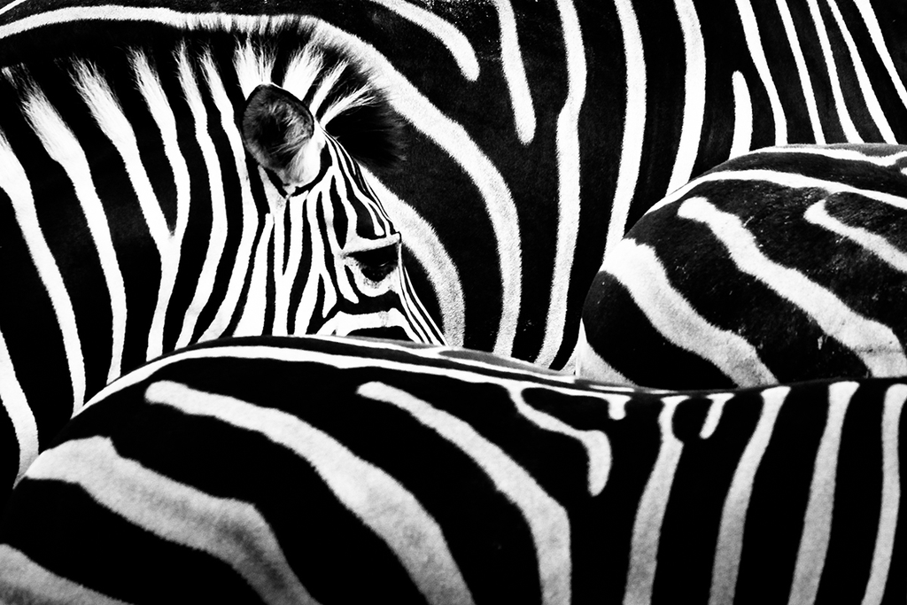

*来源*：Getty Images。

*Source*: Getty Images.

我们寻找模式。即使视觉上的混乱是彻底的，我们也不会放手。你可以自己试试。在一个阳光明媚、高空中的云沐浴着阳光的日子里，看看那些云。看看你是否能在云的形态中找到什么熟悉的东西。我打赌你能。而且我打赌一旦你找到了，你就不会放手。例如，当你在那些云中看到一张人脸、一只动物或某个怪物时，你就在视觉混沌中捕捉到了一个模式，并且不会放手。一旦是模式，永远是模式。

We seek patterns. Even when the visual chaos is complete, we will not let go. You can try this out yourself. On a sunny day when there are clouds high up in the sky basking in the sun, have a look at those clouds. See whether you find anything familiar in the configuration of clouds. I bet you do. And moreover, I bet when you do, you will not let go. When, for instance, you see a human face, an animal, or some monster in those clouds, you pick up a pattern in the visual pandemonium and will not let go. Once a pattern, always a pattern.

这些例子表明，整体常常不同于其各部分。在寻找模式时，我们把所有看起来相同的东西归为一组，把所有看起来不同的东西归为另一组。这是一件好事，否则在一场足球比赛中就不可能区分两支球队。同一支球队的颜色看起来相同，因而属于同一组。类似地，任何彼此更靠近的东西，我们都把它们归为同一组。这也是一件好事，因为它有助于你在视觉混乱中识别出斑马。这也是好事，否则你就会生活在一个支离破碎的世界里。

What these examples show is that the sum is often different than its parts. In our pattern seeking, we place everything that looks the same in one group and everything that looks different in another. This is a good thing, for it otherwise becomes impossible to distinguish one team from the other in a football match. The colors of the same team look the same and thus belong to the same group. Similarly, anything that is closer to something else we place in the same group. That too is a good thing, as it helps you in identifying zebras in visual chaos. That’s a good thing too, as you would otherwise live in a fragmented world.

对于听觉信息，情况也差不多。我们寻找熟悉的模式。让我们来看一个周五晚上的派对。DJ在播放最新的节拍，舞池里挤满了人。节拍、低音和你周围的喧闹声让你很难听清你的谈话对象。你在努力拼凑从她嘴里说出来的词。你在拼命地从那些穿过嘈杂噪声到达你耳边的信息中形成模式。或者想象一个更安静的派对，一个鸡尾酒会，在那里你能听到你的谈话对象。你仔细听她在说什么，听不到旁边的人在谈论什么（毕竟，你所有的注意力都集中在你的谈话对象身上）。然而，一旦站在你旁边的人提到你的名字，你确实会捕捉到它。<sup>5</sup>你寻找那些频繁出现因而对你来说熟悉的模式。

For auditory information, things are not much different. We seek familiar patterns. Let’s consider a party on Friday night. The DJ plays the latest beats, and the dance floor is filled. The beats, bass, and the loud noise around you make it hard to follow your conversational partner. You are trying to make up the words that are coming out of her mouth. You are desperately forming patterns out of the information that does reach you through the loud noise. Or imagine a quieter party, a cocktail party, where you can hear your conversational partner. You carefully listen to what she is saying, not hearing what the people next to you are talking about (after all, all your attention is focused on your conversational partner). And yet, as soon as the people standing next to you mention your name, you do pick it up.<sup>5</sup> You search for the patterns that are frequent and thus familiar to you.

我年轻的时候，经常听一个包含广播游戏的电台节目。节目的听众可以打电话进来参加游戏，游戏内容是辨认同时播放的两首歌。参赛者的任务是把他们听到的音乐理清楚，说出这两首歌的名字。这需要一些认真的模式匹配。参赛者必须穿透同时播放的两种节拍、已经变成一片嘈杂的歌词，以及听起来乱成一团的其他乐器。根据一首歌内部声音的相似性和接近性来理清两首歌的模式，是相当大的挑战，只有少数参赛者设法赢得了奖品：五张由你自选、寄给你的专辑。在我那个年纪，那听起来就像中了强力球彩票！

When I was younger, I often listened to a radio show that included a radio game. Listeners of the show could call in and participate in the game, which consisted of recognizing the two songs played simultaneously. The task of the contestant was to disentangle the music they heard and name the two songs. It required some serious pattern matching. Contestants had to listen through the two beats playing at the same time, the lyrics—which had become one big cacophony—and the other instruments—which sounded confused. Disentangling two patterns of songs based on similarities and proximities in sound within a song was quite a challenge, and only few contestants managed to win the prize: five albums of your choice sent to you. At my age, it sounded like winning the Powerball lottery!

尽管辨认同时播放的两首歌常常很难，但一旦你认出了歌中的模式，你就能毫无困难地唱完一首歌的剩余部分。想想看。一旦那首过去的歌响起，你会想起自己知道它，但还找不到你一直在寻找的那个模式。但一旦你找到了它，你就会开心地跟着唱，仿佛它从未离开过你的脑海。但如果没有找到旋律或歌词中的最初模式，你就会迷失。

Even though recognizing two songs played at the same time often turns out to be hard, once you recognized the patterns in the song, you would have no difficulty singing the remainder of a song. Think about it. As soon as that song of the past plays, you recall knowing it, but cannot yet find the pattern you have been looking for. But once you find it, you happily sing along as if it had never been out of your mind. But without finding the initial patterns in melody or lyrics, you would be lost.

你有多少次在唱一首歌的歌词时，后来才发现这些歌词并不完全对？你并没有完全听清那些词，而是形成了一些看起来说得通的声音组合。“Saving his life from this warm sausage tea”（从这杯热香肠茶中救他一命）（而不是皇后乐队《波西米亚狂想曲》中的“spare him his life from this monstrosity”，饶他一命，免受这怪物之害），或者“See that girl, watch her scream, kicking the dancing queen”（看那个女孩，看她尖叫，踢那个舞会皇后）（而不是ABBA《舞会皇后》中的“see that girl, watch that scene, dig in the dancing queen”，看那个女孩，看那场景，欣赏那舞会皇后），或者“Here we are now, in containers”（我们现在在这里，在集装箱里）（而不是涅槃乐队《少年心气》中的“here we are now, entertain us”，我们现在在这里，取悦我们吧）。我们被模式粘住了。而一旦你找到了一个模式，它就再也不会离开你的脑海。

How often have you been singing the lyrics of a song, only to later find out that these lyrics were not quite right? You didn’t quite hear the words but formed combinations of sounds that seemed to make sense. “Saving his life from this warm sausage tea” (rather than “spare him his life from this monstrosity” in Queen’s “Bohemian Rhapsody”) or “See that girl, watch her scream, kicking the dancing queen” (rather than “see that girl, watch that scene, dig in the dancing queen” in ABBA’s “Dancing Queen”) or “Here we are now, in containers” (rather than “here we are now, entertain us” in Nirvana’s “Smells Like Teen Spirit”). We are stuck to patterns. And once you have found a pattern, it never gets out of your head again.

在嗅觉或味觉中寻找模式也非常相似。如果我给你一杯好酒——对于不那么好的酒也一样——问你闻到和尝到了什么，你可能会回答“樱桃和其他红色水果”、“带一丝橡木味”、“一小撮肉桂”。基本上，这要求你在所体验到的气味和味道中识别出模式，并给这些模式贴上标签。而一旦你体验过某些气味或味道，以后再对这种气味和味道进行模式匹配就会变得更容易。

Finding patterns in olfaction or gustation is very similar. If I present you with a glass of good wine—but for not-so-good wine, it is no different—and ask you what you smell and taste, you might respond with “cherry and other red fruits,” “with a hint of oak,” “a pinch of cinnamon.” Basically, it requires you to identify patterns in the smells and flavors you experience and labeling these patterns. And once you have experienced some smells or flavors, it will become easier to pattern match the smell and flavor again later.

人类是伟大的模式寻找者。还是不信？我们来打几个赌！正面还是反面？我抛硬币，它正面朝上落地。我再抛一次，它又是正面朝上。我再抛一次，又是正面。你开始起疑心了。连续三次正面一定意味着有什么猫腻。如果我现在再让你选正面还是反面，你很可能会选正面。对我们大多数人来说，在硬币连续三次正面朝上之后，我们看到一个模式正在形成。而当我们看到一个模式出现时，我们就不会放手。然而，得到正面的概率与得到反面的概率一样高，当然前提是硬币本身正面或反面朝上的机会均等，而且你不是一个掌握了决定结果技巧的抛硬币专家。第一次抛硬币得到正面的概率是1/2，第二次是1/2 × 1/2。连续三次就是1/8，即12.5%。基本上，抛硬币的结果数是*n<sup>r</sup>*，其中*n*是每次抛硬币的选项数（正面或反面），*r*是抛硬币的次数。所以有八种可能的结果，三次正面是其中之一。正-正-正的结果与反-反-反的结果一样可能，也与正-反-正的结果一样可能。

Humans are great pattern seekers. Still not buying it? Let’s place some bets! Heads or tails? I flip the coin, and it lands on its head. I flip the coin again, and it lands on its head again. I flip it again, and it is heads again. You start to become suspicious. Three times in a row heads must mean something sneaky is going on. If I now ask you again to choose heads or tails, you likely choose heads. For most of us, we see a pattern emerging after the coin landing on heads three times. And when we see a pattern coming, we won’t let go. Yet chances of obtaining heads are as high as obtaining tails, assuming of course the coin allows for an equal chance of landing on its head or tail in the first place and that you are not an expert at flipping coins, having mastered the skill of determining the outcome. Chances of obtaining heads the first time you flip a coin is 1/2, and the second time it is 1/2 × 1/2. Three times in a row makes it 1/8, or 12.5 percent. Basically, the number of outcomes of the coin flipping is *n<sup>r</sup>*, where *n* is the number of options you have at each coin flip (heads or tails) and *r* is the number of times you flip the coin. So there are eight possible outcomes, where heads three times is one of them. A heads-heads-heads outcome is as likely as a tails-tails-tails outcome, and as likely as a heads-tails-heads outcome.

我们的模式匹配会采取极端的形式，甚至导致迷信。你坐在沙发上，想到你最好的朋友。你应该给她打个电话，因为你们俩已经有一阵子没聚了。然后电话响了。电话那头是你最好的朋友熟悉的声音。这不可能是巧合！在所有可能给你打电话的人中，偏偏是你最好的朋友打来了——就是你刚刚想到的那个人，在你可能想到的所有人中。这显然是心灵感应。你的朋友一定在伸手拿电话时感应到你在想她。或者在她伸手拿电话时，你一定开始想她了！但如果你再多想一点，在所有会给你打电话的人中，你的朋友是最有可能打电话的人。而在所有你可能会想到的人中，同一个朋友也是你最有可能想到的人。而且，如果你有理由想到那位朋友，那位朋友很可能也有类似的理由想到你并给你打电话。在你可能确信存在一个模式的地方，其实不过是巧合。心灵感应并没有打败科学。相反，是你的模式匹配技能忽视了科学。

Our pattern matching takes extreme forms that can even lead to superstition. You sit on the couch and think of your best friend. You should call her, because it has been a while since you two hung out. And then the phone rings. On the other end of the line is the familiar voice of your best friend. This cannot be a coincidence! Out of all the people that could have called you, your best friend calls—the one you just thought about, out of all the people you could have thought about. This is a clear case of telepathy. Your friend must have sensed you were thinking of her while she reached for the phone. Or while she reached for the phone, you must have started to think of her! But if you think a little further, of all the people who would call you, your friend is the most likely person to call. And of all the people you could think about, that same friend is most likely who you would think about. Moreover, if there is a reason for you to think about that friend, chances are that friend has a similar reason to think about you and call you. Where you may have been convinced of a pattern, there is not much more than coincidence. Telepathy has not beaten science. Instead, your pattern-matching skills ignored science.

让我们回到我在本章开头讲的数字13。想象一下今天是十三号星期五。很快又会有一个。而任何一个paraskavedekatriaphobic（十三号星期五恐惧症患者——以防这个词还没被录入你的心理词库）都知道，这是个坏消息。如果你是一个triskaidekaphobic（十三恐惧症患者——你心理词库的又一个新词），情况也好不到哪里去。

Let’s return to the number 13 that I started out this chapter with. Imagine it is Friday the thirteenth. Soon one is coming up again. And as any paraskavedekatriaphobic—those who have a fear of Friday the thirteenth, in case the word was not yet registered in your mental lexicon—knows, that is bad news. If you are a triskaidekaphobic—those who have a fear for the number 13, another word for your mental lexicon—things are not much better.

你把闹钟定在早上7点，但它没响。幸运的是你醒得不算太晚，穿好衣服，冲下楼，却发现咖啡没了。你上了车，尽管平时几乎从不堵车，现在——偏偏是在这一天——去上班的路上发生了一起事故，把你困在了堵车的车流中间。这几乎不足为奇。我们看到一个模式正在形成，而我们不会放手。

You had set your alarm for 7 a.m., but it does not go off. Luckily you wake up not too late, get dressed, rush downstairs, and find you are out of coffee. You get into your car, and even though there hardly ever is a traffic jam, now—especially on this day—there is an accident on the road to work that puts you in the middle of the traffic jam. This can hardly be surprising. We see a pattern emerging, and we won’t let go.

事实上，十三号星期五没有理由让人担心。路上的车更少，人们也往往更谨慎。但作为一个十三号星期五恐惧症患者和十三恐惧症患者，你可能会把这个证据当作支持你恐惧的证据：看，要是路上的车更多，事故数量就会更高——这清楚地证明了那个不吉利的星期五的厄运！仿佛这个模式——尽管是一个你听说过但从未真正经历过的模式——证明了你是对的，即使你是错的。因为如果你的闹钟在任何其他日子没响，你的咖啡用完了（这种事时有发生），你被困在堵车中（这种事你经常遇到），你甚至都不会想到去怪罪十二号星期四。你注意到了一个模式，并为它找到了证据。

There is, in fact, no reason to be concerned on Friday the thirteenth. There are fewer cars on the road, and people tend to be more cautious. But as a paraskavedekatriaphobic and triskaidekaphobic, you might find that evidence as evidence for your fear: see, the number of accidents would have been higher had there been more cars on the road—clear evidence for the bad luck on that unlucky Friday! It is as if the pattern, albeit a pattern you heard of but never actually experienced, proves you right, even when you are wrong. Because if your alarm had failed any other day, and you had run out of coffee (as happens every so often), and you were stuck in the traffic jam (as you so often are), you would not even have thought about blaming Thursday the twelfth. You noticed a pattern and found evidence for it.

这样的例子表明，你在寻找模式的能力上表现出色。你不仅是一个热衷的语言使用者，能够把六万多个词记在心里并以闪电般的速度加工它们，而且你还有另一种值得骄傲的能力，那就是在序列中发现模式并作出预测。例如，当看到*2*、*4*、*6*、*8*、*10*时，你能够接着写出*12、14、16*和*18*。即使变得难一点，比如*1*、*3*、*6*、*10*、*15*、*21*，你也能够接着写出*28*、*36*、*45*和*55*。你拥有的数字越多，就越容易发现模式（锚定与调整）。模式匹配技能远不止于此。很少有人会在彩票上选择*1*、*2*、*3*、*4*、*5*、*6*这几个数字，尽管用这组数字中头奖的概率与用下面这组数字中头奖的概率一样高（或者其实一样低）：*91*、*34*、*65*、*19*、*23*、*87*。再举一个例子，试着想出六个不构成序列的数字。结果发现这是一项困难的任务。你还没反应过来，就写出了*62*、*52*、*42*、*32*，陷入了一个模式。数字看腻了？我们来看看你今天的星座运势。

Examples like these show you excel in pattern-seeking abilities. Not only are you an avid language user, who is able to keep more than sixty thousand words in mind and process them with lightning speed, but you also have another ability to be proud of, that of detecting patterns in sequences and making predictions. For instance, when seeing *2*, *4*, *6*, *8*, *10*, you are able to continue with *12, 14, 16*, and *18*. And even when it gets a bit harder, as in *1*, *3*, *6*, *10*, *15*, *21*, you are able to continue with *28*, *36*, *45*, and *55*. The more numbers you have, the easier it gets to detect the pattern (anchoring and adjustment). Pattern-matching skills go much further. Very few people would choose *1*, *2*, *3*, *4*, *5*, *6* as the numbers on their lottery form, despite the fact that the chances of winning the jackpot on this number are as high (or actually as low) as winning the jackpot on the following number sequence: *91*, *34*, *65*, *19*, *23*, *87*. As another example, try to come up with six numbers that are not part of a sequence. It turns out to be a difficult task. Before you know it, you produce *62*, *52*, *42*, *32*, and you are stuck in a pattern. Bored of numbers? Let’s take a look at your horoscope for today.

> 此刻你应该允许自己用心去思考，而不是用你冷冰冰的灰质。今天，表达你的感受应该是你的首要任务。选择不费心的娱乐。你的日常生活今天会显得非常乏味，你会迫切需要一些高能量来给这一成不变的生活带来一点新鲜感。今天当有人对你说了一些令人震惊的话时，尽力保持克制、冷静的风度。现在不是感到尴尬或不愿示弱的时候，尤其是在那些因为你本来的样子而爱你的人面前。调动你那出了名的灵活性吧，因为你今天会用得上它！今天早上醒来时你相当确定自己会作出哪个选择，但随着这一天的展开，你会了解到一些可能会动摇你看法的事情。在一天的早些时候积极行动。早晨是解决最近一个误会的好时机。这一天的事件可能会在你不久的将来带来很多不确定性，但别担心——这是那种会激发你的好奇心、推动你的创造力的不确定性。今天，保持愉快、保持积极、享受乐趣对你来说是极其重要的事情——事实上，如果你想保持良好的精力，乐趣是必不可少的。

> Right now you should allow yourself to think with your heart instead of your cold gray matter. Today, communicating your feelings should be your top priority. Go for low-maintenance entertainment. Your everyday routine will seem very stale today, and you’re going to be in desperate need of some high energy to bring a bit of freshness to the same old same old. Do your best to maintain a controlled, calm demeanor when someone says something shocking to you today. This is no time to feel embarrassed or reluctant to be vulnerable, especially with people who love you for who you are. Call up some of your famous flexibility, because you are going to need it today! You woke up this morning pretty sure of which choice you would make, but as this day continues to unfold, you will learn a few things that might sway your opinion. Be active early in the day. The morning is a good time to resolve a recent misunderstanding. This day’s events could create a lot of uncertainty in your near future, but don’t worry—it’s the type of uncertainty that stimulates your curiosity and drives your creativity. Being cheerful, staying positive, and having fun are extremely important undertakings for you today—in fact, fun is vital if you want to keep good energy levels.

看起来是一份完美的星座运势。你应该开始用心去感受，你的日常生活确实需要一些新鲜感，你需要变得更灵活一点，而你今天面临的不确定性会帮助你激发好奇心，最后是最好的建议：乐趣对你的生活至关重要。然而，问题在于我不知道你的星座，也不可能知道你是在哪一天、哪一月或哪一年读你的星座运势的。相反，上面呈现的星座运势是由我写这段文字时所有十二个星座运势中的句子拼凑而成的。从一个星座运势中我取了第一句，从另一个中取了第二句，再从下一个中取了第三句，依此类推。因此上面呈现的星座运势并不存在，或者更确切地说，它是所有星座运势的大杂烩。毫无疑问，你在上面的星座运势中认出了自己。这种认同并不令人惊讶，原因在于星座运势的模糊性，但更重要的是，在于你在自己与所陈述内容之间认出的模式。

Looks like a perfect horoscope. You should start feeling with your heart, your everyday routine does need some freshness, you need to become a bit more flexible, and the uncertainty you are facing today would help you with your curiosity, concluding with the best advice: Fun is vital for your life. The problem, however, is that I do not know your zodiac sign, and I cannot know what day, month, or year you are reading your horoscope. Instead, the horo-scope presented above is a collection of sentences from all twelve horoscopes the moment I am writing this. For one horoscope, I took the first sentence, from another the second, the next one the third, and so on. The horoscope presented above thus does not exist, or rather, it is a mashup of all horoscopes. Undoubtedly you recognized yourself in the horoscope above. That recognition is not a surprise because of the ambiguity of the horoscope, but more importantly, because of the patterns you recognize between you and what is stated.

## 更多谬误

## MORE FALLACIES

让我向你呈现一些简单的选择题，就是你在高中和大学里非常熟悉的那种——简单而基本的问题，你肯定一下子就知道答案。我所要求的只是给这六道题中的每一道圈出正确答案。开始吧。

Let me present you with some easy multiple-choice questions, the ones so familiar to you from high school and college—simple and basic questions you undoubtedly readily have the answer to. All I am asking is to circle the right answer for each of these six questions. Go for it.

1. 什么是角马（gnu）？  
   What is a gnu?
   1. 一种蛇  
      a kind of snake
   2. 一种鸟  
      a kind of bird
   3. 一种羚羊  
      a kind of antelope
   4. 一种鱼  
      a kind of fish
2. 第一个登上月球的人是谁？  
   Who was the first man on the moon?
   1. 路易斯·阿姆斯特朗  
      Louis Armstrong
   2. 埃隆·马斯克  
      Elon Musk
   3. 尼尔·阿姆斯特朗  
      Neil Armstrong
   4. 约翰·杨  
      John Young
3. 煮一个全熟的鸡蛋要多长时间？  
   How long should you boil a hard-boiled egg?
   1. 2分钟  
      2 minutes
   2. 6分钟  
      6 minutes
   3. 12分钟  
      12 minutes
   4. 40分钟  
      40 minutes
4. 肯尼亚有多少人口？  
   How many people live in Kenya?
   1. 1250万  
      12.5 million
   2. 3750万  
      37.5 million
   3. 5250万  
      52.5 million
   4. 7250万  
      72.5 million
5. 气压计测量什么？  
   What does a barometer measure?
   1. 太阳活动  
      Solar activity
   2. 湿度  
      Humidity
   3. 大气压  
      Atmospheric pressure
   4. 露水  
      Dew
6. 这四个城市中哪个最大？  
   Which is the largest of these four cities?
   1. 上海  
      Shanghai
   2. 圣保罗  
      Sao Paulo
   3. 德里  
      Delhi
   4. 孟买  
      Mumbai

我想这些问题并不太难。靠一些猜测，你很可能全答对了。但我猜你在第4题上开始犹豫了。在第6题上，你也犹豫了。尽管这次选择题测试，就像任何其他选择题测试一样，完全可能连续六次都以第三个选项为正确答案，你很可能不愿意掉进这个模式里。你基本上成了研究者所说的赌徒谬误的受害者。你怀疑在答案应当随机的情况下，是否可能四次都是同一个答案。而当所有答案都对应同一个字母时，你开始感到不安。那不可能是对的。现在一定会出现另一个答案来打破这个模式。赌徒谬误这个名字来自轮盘赌桌上的赌徒。在轮盘上连续出现一系列红色之后，赌徒对再次出现红色的预期会降低。你看到一连串的红色——或者选择题的答案选项——你就会认为——违背一切逻辑——出现黑色比再出现一次红色会构成一个更常见的序列。

The questions were not too difficult, I suppose. And with some guesswork, you probably got them all correct. But I guess you started to hesitate on question 4. And with question 6, you also hesitated. Even though this multiple-choice test, like any other multiple-choice test, could have the third choice as the right answer six times in a row, you were probably reluctant to fall for that pattern. You basically fell victim to what researchers have called the gambler’s fallacy. You wondered whether four times the same answer would be possible with presumably randomized answers. And when all answers were linked to the same letter, you started to feel uncomfortable. That cannot be right. There must be another answer coming up now that breaks the pattern. The name gambler’s fallacy comes from gamblers at the roulette table. After a series of reds on the roulette table, the gambler’s expectation of another red decreases. You see a number of reds in a row—or multiple-choice answer options—and you think—against all logic—that the occurrence of black will result in a more common sequence than the occurrence of an additional red.

赌徒谬误是讽刺性的。因为如果你最喜欢的篮球队的投手一次又一次地得分，你就不会想到赌徒谬误，而是会想他手感正热。你会认为所有的运气都在他那边，而他之前得分这一事实提高了你对他再次得分的预期。如果你最喜欢的球员连续三次在三分线外得分，你就会指望第四次、第五次和第六次也会发生。因为在篮球的例子中你有控制的错觉（毕竟，你每场比赛都穿的那件幸运衫一定起了作用！），你就容易陷入热手谬误。而知道你在选择题测试中没有（控制的错觉），你就想避免陷入赌徒谬误，避免陷入你眼前看到的模式。

Gambler’s fallacy is ironic. Because if the shooter of your favorite basketball team were scoring time after time, you would start thinking not about gambler’s fallacy but about him having a hot hand. You would think all the luck was with him, and the fact that he scored earlier increases your expectation that he will score again. If your favorite player scored from behind the three-point line three times in a row, you would just count for it to happen the fourth, fifth, and sixth time. Because you have the illusion of control in the basketball example (after all, that lucky shirt you wear every match must have made the difference!), you fall prone to the hot hand fallacy. Knowing that you don’t have the (illusion of) control with the multiple-choice test, you want to avoid falling for the gambler’s fallacy, for the pattern you see in front of you.

## 结构原则

## PRINCIPLES OF STRUCTURE

在二十世纪早期，一群心理学家定义了一些具体的原则，我们用这些原则在所感知的信息中形成模式。<sup>6</sup>他们甚至把这些原则称为“定律”。例如，我们在左边的图中看到四组，每组三个圆。

In the early part of the twentieth century, a group of psychologists defined specific principles we use to form patterns in the information we perceive.<sup>6</sup> They even called these principles “laws.” For instance, we see four groups of three circles in the picture on the left.

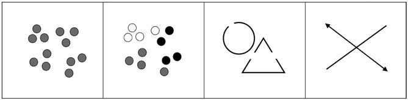

**接近律、相似律、闭合律、连续律**

**Laws of Proximity, Similarity, Closure, Continuation**

这很奇怪，因为只有十二个圆，但我们把它们分组，而且是根据它们的接近程度来分组的。彼此更靠近的圆被感知为属于同一组。另一条原则表明，如果物体看起来相似，我们往往会把它们聚在一起，就像左边第二张图那样。我们把白色的圆聚在一起，把灰色的圆聚在一起，把黑色的圆聚在一起（除非你按它们的接近程度来聚类而忽略它们颜色上的相似性）。在左边第三张图中，我们运用把未闭合的东西闭合起来的原则，就像那个圆一样。或者，我们不会识别出一个巨大的插入符号放在三条相连的线上面，而只是看到一个三角形。而在最右边，我们倾向于看到连续的线，而不是两条各带一个90度角的箭头线。我们不喜欢中断；我们追求完整、整体、闭合和连续。

That is odd, because there are just twelve circles, but we group them, and we group them on the basis of their proximity. Those circles that are closer to one another are perceived as belonging to the same group. Another principle suggests that if objects look similar, we tend to cluster them together, as in the second picture from the left. We cluster the white circles, cluster the grey circles, and cluster the black ones (unless you cluster by their proximity and ignore their similarity in color). And in the third picture from the left, we use the principle of closing something that is not closed, as in the circle. Or rather than identifying a massive caret on top of three lines that are attached, we simply view a triangle. And to the far right, we tend to see continued lines rather than two arrow lines, each one with a 90-degrees angle in it. We don’t like interruptions; we go for completeness, totality, closure, and continuation.

为形状和颜色知觉所定义的原则似乎也适用于语言。例如，当你读这些页面上的词时，你依靠接近性来把词分开。字符的接近性帮助你识别句子中的词。对于段落，你也是这样做的。扫一眼这一页，段落之间被空白很好地标示出来。或者反过来，没有被空白分隔开的东西显然属于同一个单位。对于声音也是如此。尽管某人的语流听起来可能是不间断的，但在句子之间——如果词与词之间还没有的话——可以找到微小的停顿。根据各条信息彼此之间的接近程度来组织信息是有帮助的。

The principles defined for the perception of shapes and color also seem to apply to language. For instance, while you are reading the words of these pages, you are relying on the proximity to keep the words apart. The proximity of the characters helps you identify the words in a sentence. And you do the same thing with paragraphs. When glancing over this page, the paragraph breaks are nicely marked by space. Or reversely, what is not separated by space apparently belongs to the same unit. And this is no different for sounds. Even though somebody’s speech stream may sound uninterrupted, tiny little pauses—if not already really small ones between words—can be found between sentences. It helps to organize pieces of information on the basis of how close these pieces are in relation to one another.

而对于基于相似性的分组，情况也差不多。在最基本的层面上，你假设看起来或听起来相似的词属于同一组。相似律（Law of Similarity）和接近律（Law of Proximity）一定属于定律这一组，因为它们看起来（或听起来）相同。但我们可以再进一步。我们甚至可以说，较短的词往往在性质上更偏语法性，而较长的词往往更有意义。确实，像*for*、*the*、*of*、*are*、*not*、*much*、*at*、*the*、*that*和*and*这样的短词，都往往是语法胶水，而不是有意义的项目。另一方面，像*similarity*（相似性）、*things*（事物）、*different*（不同的）、*basic*（基本的）、*level*（层面）和*assume*（假设）这样的词看起来更长，我们可以把较长的词归入比较短的词更有意义的那一组。这听起来牵强吗？也许，但无论如何，值得注意的是，短词在性质上往往是语法性的，而较长的词在性质上往往是词汇性的。那么对于我们这些模式寻找者来说，不捕捉到这种分组就很奇怪了。如果词汇项和语法项的分组听起来有些牵强，那就让我再牵强一点。我们来考虑一种按意义的分组。让我提到一个男人和一个女人；他七十五岁，她七十四岁。他喜欢园艺，她热爱设计。他们俩一起享受着宁静的生活。根据意义上的相似性（*男人*—*他*；*女人*—*她*；*男人和女人*—*他们*），你已经把这些词聚成了组。

And for grouping on the basis of similarity, things are not much different. At the most basic level, you assume that words that look or sound similar belong to the same group. The Law of Similarity and the Law of Proximity must belong to the group of laws because they look (or sound) the same. But we can take things a step further. We could even state that the words that tend to be short tend to be more grammatical in nature, whereas the words that tend to be longer tend to be more meaningful. And indeed, short words such as *for*, *the*, *of*, *are*, *not*, *much*, *at*, *the*, *that*, and *and*, all tend to be grammatical glue rather than meaningful items. On the other hand, words like *similarity*, *things*, *different*, *basic*, *level*, and *assume*, are words that look longer, and we could cluster longer words to the group of being more meaningful than shorter words. Does that sound like a stretch? Maybe, but in any case, it is worth noting that short words tend to be grammatical in nature, whereas longer words tend to be lexical in nature. It would then be awkward for us, the pattern seekers, not to pick up on this grouping. And if the lexical and grammatical item groupings sounded like a stretch, let me stretch things a bit further. Let’s consider a grouping by meaning. Let me mention a man and a woman; he is seventy-five, and she is seventy-four. He likes gardening, and she loves designing. They both enjoy a quiet life together. On the basis of similarities in meaning (*man*—*he*; *woman*—*she*; *man and woman*—*they*), you have clustered the words in groupings.

我们还看到，如果我们感知的物体有一个断口，我们往往会把这个物体感知为一个整体，就像那些“断开的”圆和三角形那样。这一原则也可以应用于语言。你可能在一页的末尾体验到这一点。你正在读一个句子，读着读着它的词，你突然——。确实，你突然到达了页面的末尾，或者在这个例子中，句子的末尾。而没有句子的闭合，感觉就是不对劲。你需要闭合。还有连续。我可以开始一个句子，被另一个句子打断，但继续原来的句子。在口语中，连续的力量甚至更强。当有人在和你说话，说到半句时被一声咳嗽打断，咳嗽并不会打断这个句子。尽管有咳嗽，你仍然会考虑这个句子的延续。

We also saw that if there is a break in an object we perceive, we tend to perceive the object as a whole, as was the case in the “broken” circles and triangles. This principle can also be applied to language. You may experience this at the end of a page. You are reading the sentence, and while you are reading its words you suddenly—. Indeed, you suddenly have reached the end of the page, or the sentence in this example. And without the closure of a sentence, it simply does not feel right. You need closure. And continuation. I can start a sentence, interrupted by another one, but continue the original sentence. In spoken language, the power of the continuation is even stronger. When somebody talks to you, and halfway through the sentence, they are interrupted by a cough, the cough does not interrupt the sentence. You consider a continuation of the sentence despite the cough.

许多这样的例子已经在第3章（“猜测”）中呈现过，当时语言加工被描述为作出有根据的猜测。我们现在可以加上“基于所感知模式的有根据的猜测”。

Many of these examples were already presented in chapter 3 (“Guess”), when language processing was described as making educated guesses. We can now add “educated guesses based on perceived patterns.”

## 人类与其他动物

## HUMANS AND OTHER ANIMALS

人类是模式寻找者。其他物种呢？它们不擅长寻找模式吗？显然它们擅长。遵循到目前为止所呈现的组织原则的肯定不只是人类。动物也是——也许不太是语言的组织原则，但肯定是知觉信息的组织原则。例如，研究者给猫看视频，视频中有四个吃豆人形状的扇形圆盘在旋转（见下一页）；其中一帧看起来像左边那张图。<sup>7</sup>

Humans are pattern seekers. What about other species? Don’t they excel in finding patterns? Clearly they do. It is certainly not only humans who follow the organization principles presented so far. Animals do too—perhaps not so much organizational principles for language, but certainly organizational principles for perceptual information. For instance, cats were shown videos in which four Pac-Man sectored discs rotated (see the next page); one of the frames looked like the one on the left.<sup>7</sup>

[figure not shown]

圆盘在旋转，但偶尔会构成一个错觉的正方形，就像上面右边那张图那样。错觉正方形出现的那一刻，猫就会得到食物。这些猫很快就弄清了这个模式。显然，它们已经学会了正方形的主观轮廓，从而掌握了这条组织原则。正方形并不真的在那里，但轮廓可以从形状中被构造出来。当形状——三角形和正方形——呈现在网格背景上时，仓鸮也展示了它们的主观轮廓技能。<sup>8</sup>猫头鹰毫不费力地察觉到这些形状，啄两个键中的一个，并得到一个自动喂食器送出的奖励。而在你开始注意到一个模式、得出结论说知觉组织原则只适用于夜行性捕食者之前——猕猴也通过了测试。<sup>9</sup>

The discs rotated, but once in a while they configured to an illusionary square, as in the picture on the right above. The moment the illusionary square emerged, the cats received food. It took these cats very little time to figure out the pattern. Apparently, they had learned the subjective contour of a square, and this mastered the organizational principle. The square was not really there, but the contours could be made up from the shapes. Barn owls also showed their subjective contours skills when shapes—triangles and squares—were presented against a grated background.<sup>8</sup> The owls had little difficulty detecting the shapes and pecked one of two keys and were given rewards delivered by an automated feeder. And before you start noticing a pattern and draw the conclusion that the principles of perceptual organization apply to nocturnal predators only, macaque monkeys also passed the test.<sup>9</sup>

有大量且日益增多的文献表明，动物善于发现模式并作出预测。自20世纪80年代以来，动物认知领域<sup>10</sup>已经向我们表明，引用灵长类动物学家和动物行为学家弗兰斯·德瓦尔的书名，“我们是否聪明到足以知道动物有多聪明”这个问题<sup>11</sup>是完全合理的。德瓦尔报告了黑猩猩向它们所爱的同伴告别，因此意识到未来的分离；或者黑猩猩屏住呼吸等待被挠痒；或者黑猩猩逃出笼子，在半夜跑过走廊，但在结束冒险回来时，小心地在身后关上门，这样就没人会发现——只是它们忘了清理走廊里的粪便。

There is a large and growing body of literature that demonstrates that animals are good at finding patterns and making predictions. Since the 1980s, the field of animal cognition<sup>10</sup> has shown us that the question of whether we are smart enough to know how smart animals are,<sup>11</sup> to cite the title of primatologist and ethologist Frans de Waal, is fully justified. De Waal reports chimpanzees saying goodbye to their loved ones, thus being aware of the future separation, or chimps holding their breath awaiting being tickled, or chimps escaping their cage, running through the hallways in the middle of the night, but upon returning from their escapade, carefully closing the door behind them so nobody would find out—except that they had forgotten to remove their droppings from the hallway.

或者再举德瓦尔给出的另一个例子，丽萨拉（Lisala）的例子，她是一只倭黑猩猩，生活在刚果民主共和国金沙萨附近的一个丛林保护区。丽萨拉——她的宝宝紧紧抓着她的下背部——肩上扛着一块十五磅重的石头。她扛着这个沉重的负担走了半英里。然后她停下来，拿起石头，把它当作大锤，砸开散落在一块石板上的一些非常坚硬的坚果。砸开所需的坚果后，她把石头留在那里，带着宝宝回去了。这些以及其他例子都为黑猩猩有计划的社会策略提供了证据，为合作、利他、欺骗、冲突解决和共情提供了证据。这些例子都表明，动物是聪明的，它们以模式思考，也会思考未来——就像人类一样。

Or take another example de Waal gives, that of Lisala, a bonobo living in a jungle sanctuary near Kinshasa in the Democratic Republic of the Congo. Lisala—with her baby clinging to her lower back—carried a heavy fifteen-pound rock on her shoulders. She walked with the heavy burden on her shoulders for half a mile. Then she stopped, took the rock, and used it as a sledgehammer on some very tough nuts that were lying around in a slab of rock. After having cracked the nuts she needed, she left the rock behind and returned with her baby. These and other examples all provide evidence for planned social strategies in chimps, evidence for cooperation, altruism, deception, conflict resolution, and empathy. These examples all show that animals are smart, think in patterns, and think about the future—just like humans.

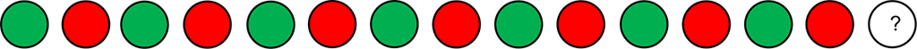

这似乎不太难。在这个序列中，绿灯和红灯交替出现，所以每个绿灯之后你可以预期一个红灯，而每个红灯之后，嗯，是一个绿灯。所以答案是浅灰色。你的模式匹配技能没有让你失望。现在我们来试另一个序列。

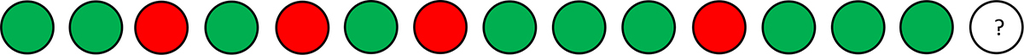

现在，在喂食器上方、老鼠视线之外，安装了一些灯。当喂食器里有食物时，这些灯就会亮起，左边喂食器75%的时间亮，右边喂食器25%的时间亮，但在左右喂食器之间随机切换。耶鲁大学的本科生被允许看老鼠跑迷宫，并被允许事先看到灯亮起，这样他们甚至在老鼠拿到食物之前就能预料老鼠是否选对了路。经过一系列试次后，学生们被要求预测下一次食物会从哪里出来。

Now above the feeder, out of the rat’s eyesight, lights were placed. These lights turned on when the feeder contained food, 75 percent of the time for the left feeder, 25 percent for the right feeder, but switching between left and right feeder randomly. Undergraduate students at Yale University were allowed to see the rats running through the maze and were allowed to see the lights turning on before, so they could anticipate whether the rat chose the right path even before it got the food. After a series of trials, the students were asked to predict where the food would come from next.

老鼠总是选择左边的喂食器，但学生们没有。相反，他们使自己选择的相对频率与喂食器释放食物的相对频率相匹配，因此75%的时间选择左边的喂食器。这很奇怪，因为显然学生们没有选择最优解。原因如下。用老鼠采取的最大化方法得到食物的概率是75%，即它们选择左边喂食器的时间百分比乘以左边喂食器释放食物的时间百分比（1.0 × 0.75 + 0 × 0.25 = 0.75）。然而，非老鼠（我们称之为人类）采取了概率匹配的方法，这只给了他们62.5%的成功率（0.75 × 0.75 + 0.25 × 0.25 = 0.625）。因此，与其说是在知觉组织方面（即我前面定义的那些原则），不如说是在模式方面，我们发现了动物行为与人类行为之间的差异：老鼠通常会选择使其成功最优化的选项，而人类则选择一种表现较差但与概率相匹配的解决方案。人类在嗅探模式，老鼠在嗅探食物。而且不仅老鼠在表现上击败了人类，鸽子也击败了人类。<sup>15</sup>

The rats always chose the left feeder, but the students didn’t. Instead, they matched the relative frequency of their choices to the relative frequencies of the feeders releasing food, and thus chose the left feeder 75 percent of the time. That is odd, because apparently the student did not go for the optimal solution. Here is why. The chance of getting food by using the maximizing approach the rat took is 75 percent, namely, the percentage of time that they chose the left feeder times the percentage of time the left feeder was releasing food (1.0 × 0.75 + 0 × 0.25 = 0.75). The nonrats (the humans, as we call them), however, went for a probability-matching approach, which only gave them a success rate of 62.5 percent (0.75 × 0.75 + 0.25 × 0.25 = 0.625). Therefore, not so much with perceptual organization, the principles I defined earlier, but with regards to patterns, we find a difference between animal behavior and human behavior, rats typically going for a choice that optimizes their success, and humans going for a solution that yields inferior performance but matches the probability. Humans were sniffing for patterns, rats for food. And not only did rats beat humans in their performance, but pigeons did also.<sup>15</sup>

## 左半球与右半球

## LEFT AND RIGHT HEMISPHERES

神经科学教授迈克尔·加扎尼加令人瞩目的学术生涯中，有很大一部分致力于研究裂脑患者。<sup>16</sup>在这些患者身上，连接左右半球的纤维束——胼胝体——已被切除。例如，这些患者曾患有癫痫发作，通过切除左右半球之间的通信通道，始于一个半球的神经混乱就可以被限制在那一个半球内，而不会扩散到整个大脑、包括两个半球。

A large part of the impressive academic career of Michael Gazzaniga, a professor of neuroscience, is dedicated to studying split-brain patients.<sup>16</sup> In these patients, the corpus callosum, the band of fibers that connects the left and right hemispheres, has been removed. These patients, for instance, suffered from epileptic seizures, and by removing the communication channel between the left and right hemisphere, the neural chaos that started in one hemisphere could be constrained to that one hemisphere and not spread over the entire brain, including both hemispheres.

裂脑患者使加扎尼加及其团队得以研究两个半球的作用。对于我们这些非裂脑患者来说，我们的大脑知道我们的身体在做什么。当我们用左手打响指时，我们知道；当我们用右手这样做时，我们也知道。对于裂脑患者来说，情况并非如此。由于我们身体与大脑的交叉连接——左臂和左腿的运动激活我们的右半球，反之亦然；右半球的激活移动我们的左臂和左腿（事实上是我们身体的整个左侧），反之亦然——如果把信息呈现给一个半球而不呈现给另一个半球，裂脑患者会怎样？

The split-brain patients allowed Gazzaniga and his team to investigate the role of the two hemispheres. Whereas for us, non-split-brain patients, our brain knows what our body is doing. When we snap our fingers with our left hand, we know, and when we do this with our right hand, we know. For split-brain patients, this is not the case. Because of the cross-wiring of our body and our brain—movement with our left arm and leg activates our right hemisphere and vice versa, and activation in our right hemisphere moves our left arm and leg (and in fact, our entire left side of our body) and vice versa. What would happen to a split-brain patient if information is presented to one and not the other hemisphere?

当加扎尼加和他的团队在一组裂脑患者身上研究这个问题时，他们向其中一名患者呈现了两张图片<sup>17</sup>：一张鸡爪的图片呈现在右视野，因而由左半球加工。一张雪景的图片呈现在左视野，由右半球加工。接下来，在患者面前呈现一组两个视野都能看到、因而由两个半球都能加工的图片。左手指向了铁锹，这并不奇怪，因为右半球加工了雪景。右手指向了鸡，这也不奇怪，因为左半球看到了鸡爪。当被问到为什么选择这些物品时，由左半球语言中枢产生的回答是：“哦，这很简单。鸡爪和鸡是一起的。”然后，看着他指向铁锹的手，他说：“而你需要一把铁锹来清理鸡舍。”左半球显然对情境作了解释，事后提供了一个符合情境的答案。左半球的大脑找到了一个模式，从无意义的信息中得出了意义，并坚持它。

When Gazzaniga and his team investigated this question with a group of split-brain patients, they presented one of them with two pictures<sup>17</sup>: A picture of a chicken claw was presented to the right visual field, thus processed by the left hemisphere. A picture of a snow scene was presented to the left visual field and was processed by the right hemisphere. Next the patient was presented with a set of pictures in front of him that could be seen by both visual fields and thus processed by both hemispheres. The left hand pointed to the shovel, not surprisingly, given that the right hemisphere had processed the snow scene. The right hand pointed at the chicken, not surprising either given that the left hemisphere had seen the chicken claw. When the patient was asked why he had chosen these items, the response, generated by the language centers in the left hemisphere, was: “Oh, that’s simple. The chicken claw goes with the chicken.” Then, looking at his right hand pointing at the shovel, he said: “And you need a shovel to clean out the chicken shed.” The left hemisphere had apparently interpreted the situation, providing post hoc an answer that fit the circumstances. The left-hemispheric brain had found a pattern, made sense out of senseless information, and stuck to it.

这种事后寻找意义的活动——加扎尼加称之为左脑*解释器*——在几项研究中得到了证明。另一名患者的左视野（右半球）被呈现了*bell*（钟）这个词，右视野（左半球）被呈现了*music*（音乐）这个词。然后呈现一系列图片，患者在四张乐器图片中挑出了画着钟楼的那一张。<sup>18</sup>当被问到为什么选了钟时，他回答说他来的路上一定听到了钟声。左脑解释器又一次编了一个故事。或者，当向一名患者呈现*red*（红色）和*banana*（香蕉）这两个词时——*red*给左半球，*banana*给右半球——患者从一些彩色笔中拿起一支红笔，画了香蕉。<sup>19</sup>当被问到为什么选红笔、为什么用左手画时，他对情境作了解释，说用左手往下拉更容易。同样，似乎是左半球试图在一个大脑认为不稳定的环境中找出意义。

This post-hoc making-sense activity, the left-brain *interpreter* as Gazzaniga called it, was demonstrated in several studies. Another patient was presented with the word *bell* to the left visual field (the right hemisphere) and the word *music* to the right visual field (the left hemisphere). A series of pictures was then presented, and the patient picked among four pictures with musical instruments the one with a bell tower depicted on it.<sup>18</sup> When he was asked why he picked the bell, he answered that he must have heard a bell ringing on his way over. Once more, his left-brain interpreter made up a story. Or when the words *red* and *banana* were presented to a patient, *red* to the left hemisphere, *banana* to the right, the patient picked up a red pen among a number of colored pens and drew the banana.<sup>19</sup> When he was asked why he had chosen the red pen and was drawing with his left hand, he interpreted the situation and argued that it was easier to pull down with his left hand. Again, it seemed as if the left hemisphere tried to make sense out of an environment that the brain considered to be unstable.

如果左半球有一个解释器，那右半球呢？在一系列实验中，加扎尼加和他的团队发现，右半球比左半球更善于拒绝那些与所呈现材料相似但不相同的图片和词语。<sup>20</sup>与左半球相比，右半球在线条画和面孔图片以及测试词方面表现出更优的记忆表现。例如，当在一项记忆任务中向一名裂脑患者呈现一个包含*apple*（苹果）和*peach*（桃子）（但不包含*plum*，李子）的词表时，左半球比右半球更可能错误地声称*plum*曾被呈现过。看起来右半球创造了一份对过去的准确记录，而左半球则在虚构和猜测。左半球似乎在为语言和认知世界寻找意义，而一个右半球解释器则在为视觉空间世界寻找意义。看起来右半球在视觉上比左半球更聪明。它擅长所谓的真实知觉，即准确地感知世界，正确地看到和记住刺激。左半球更擅长为认知和语言世界寻找意义。<sup>21</sup>它不一定非得准确，只要对一条认知捷径来说说得通就行。

If the left hemisphere has an interpreter, what about the right hemisphere? In a series of experiments, Gazzaniga and his team found that the right hemisphere was better than the left hemisphere at rejecting pictures and words that were similar but not the same as the presented materials.<sup>20</sup> Compared to the left hemisphere, the right hemisphere showed superior memory performance for line drawings and pictures of faces, as well as test words. For instance, when a split-brain patient in a memory task was presented with a list of words that included *apple* and *peach* (but not *plum*), the left hemisphere was more likely than the right hemisphere to incorrectly state that *plum* had been presented. It seems that the right hemisphere created an accurate record of the past, whereas the left hemisphere confabulated and guessed. The left hemisphere seems to make sense of the linguistic and cognitive world, while a right-hemisphere interpreter is making sense of the visuospatial world. It seems the right hemisphere is visually more intelligent than the left. It is good at what is called veridical perception, perceiving the world accurately, correctly seeing and remembering stimuli. The left hemisphere is better at making sense of the cognitive and linguistic world.<sup>21</sup> It does not so much have to be accurate, as long as it makes sense for a cognitive shortcut.

## 稳定与不稳定的环境

## STABLE AND UNSTABLE ENVIRONMENTS

那么让我们回顾一下。人类是伟大的模式寻找者。他们似乎使用不同的原则来组织所接触到的信息，而这些原则也可能适用于阅读和聆听语言。但人类在数据中寻找模式方面不一定更出色。当其他动物接受寻找模式能力的测试时，它们表现出某种相似的表现。事实上，它们也善于预测未来，至少倭黑猩猩、黑猩猩、西丛鸦、乌鸦和海豚是这样。说到闭合律或连续律，猫和仓鸮也做得很好。<sup>22</sup>

So let’s recap. Humans are great pattern seekers. They seem to use different principles in organizing the information they are exposed to, and these principles may also apply to reading and hearing language. But humans are not necessarily better at finding patterns in data. When other animals are tested on their pattern-finding abilities, they show a somewhat similar performance. In fact, they too are good at predicting the future, at least bonobos, chimpanzees, Western scrub jays, crows, and dolphins do. Cats and barn owls do well when it comes to the law of closure or the law of continuity.<sup>22</sup>

但说到在信息序列中寻找意义，人类与动物就非常不同了。动物采取更好的最大化方法，而人类则采取模式匹配。而且，模式匹配能力——导致次优表现——位于左半球，而最大化能力似乎在右半球更为突出。然而，人类只有在环境不稳定时才会进行模式匹配。当环境稳定时，他们乐于采取最大化方法。最后，模式匹配而非最优化——左半球负责模式匹配，右半球负责最大化——以及在不稳定环境中进行模式匹配而在稳定环境中进行最大化，可以在人类身上找到，但尤其是在四岁以上的人类身上。我们擅长猜测、虚构、推理、幻想和解决问题。而我们尤其擅长用左半球做这些事。

But humans very much differ from animals when it comes to finding meaning in sequences of information. Whereas animals go for the better maximizing approach, humans go for pattern matching. Moreover, the pattern-matching ability—resulting in suboptimal performance—lies in the left hemisphere, whereas the ability to maximize seems more prominent in the right hemisphere. However, humans only pattern match when the environment is unstable. When the environment is stable, they are happy to take the maximizing approach. Finally, pattern matching rather than optimizing—left hemisphere for pattern matching, right hemisphere for maximizing—and pattern matching in an unstable environment but maximizing for a stable environment can be found in humans, but particularly in humans older than four years of age. We are good at guessing, confabulating, making inferences, fantasizing, and solving problems. And we are particularly good at doing that with our left hemisphere.

## 迄今为止的模式

## THE PATTERN SO FAR

在本章即将结束之际，你可能不仅在本章中、也在本书中寻找一个模式。让我来扮演你左半球里的解释器，帮你建立这个模式。语言提供了一个相当不稳定的环境；儿童大约在四岁时变得能流利使用语言；动物似乎没有像我们这样复杂（或者更确切地说不稳定）的语言系统。而在两个半球中，语言主要在左半球加工。就像我们在本章开头讲的美元纸币、亚伯拉罕·林肯和约翰·F. 肯尼迪一样，模式匹配与语言技能之间的这些关联可能是巧合。但我不认为它们是巧合。

As we reach the end of this chapter, you might be looking for a pattern not only in this chapter but also in this book. Let me play the interpreter in your left hemisphere and help you establish that pattern. Language provides a rather unstable environment; when children are about four years old they become fluent in language; animals do not seem to have a language system as complex (or rather unstable) as ours. And of the two hemispheres, language is primarily processed in the left hemisphere. Like the dollar bill, Abraham Lincoln, and John F. Kennedy we started the chapter out with, these associations between pattern-matching and language skills may be a coincidence. But I don’t think they are.

我们以这样一个观察开始本书：人类能够把六万多个词记在心里。随后，对“我们如何能够把那些词记在心里”这一问题答案的探寻，把我们带上了一段通往四种解释的旅程，每种解释用一章来讨论。我们以训练作为答案开始了这段旅程，强化引导我们使用语言。旅程以语言本能作为把那些词记在心里的答案继续下去，其论点是我们之所以有语言天赋，是因为我们有语言本能。我们考察了一个把输入和输出结合在一起、随时间学习、并能解释加工速度的神经网络。我们还考虑了接地作为把那些词记在心里的一种解释，意义产生于知觉模拟。显然，这些答案都不应被完全摒弃，因为训练、本能、网络和接地在某种程度上都是语言加工所需要的。类似地，这些答案都不应被视为相互排斥的。更有可能的是，这些解释的某种组合构成了语言习得和语言加工的答案。

We started out this book with the observation that humans are able to keep over sixty thousand words in mind. The quest for the answer on how we are able to keep those words in mind, then, put us on a journey to four explanations, each addressed in four chapters. We started the journey with the training as an answer, with reinforcement guiding us to use language. The journey continued with a language instinct being an answer to keeping those words in mind, with the argument that we have a knack for language because we have the instinct for it. We looked at a neural network that brings input and output together, learns over time, and explains the speed of processing. And we considered grounding as an explanation for keeping those words in mind with meaning arising out of perceptual simulations. Obviously, none of these answers should be entirely dismissed, as training, instinct, network, and grounding are somehow needed in language processing. Similarly, none of these answers should be considered mutually exclusive. It is far more likely that a combination of these explanations form an answer to language acquisition and language processing.

但问题在于，每当我们遇到一项认知任务时，我们首先会走认知捷径去得出答案。这意味着我们常常把答案弄错，并被鸽子和黑猩猩超越。而这对任何关于我们如何能够把那些词记在心里的解释都构成了一个问题。如果我们无法或不愿意哪怕旋转一张简单的图片、准确地数出一个句子中的字符数、得出一些逻辑结论、或者估计一个简单序列中的概率，或者以其他方式走最容易的路以免浪费任何认知能量，那么我们就应该再次挠挠头，思考一下走认知捷径（在包括语言任务在内的一系列认知任务上结果远非令人印象深刻）与我们迄今讨论过的四种解释之间的矛盾。那么，我们如何解释在如此多认知任务上的惨败与在语言加工这一语言认知任务上的惊人成功之间的矛盾呢？

But the problem is that whenever we encounter a cognitive task, we first take a cognitive shortcut to the answer. This means we commonly get the answer wrong and get outperformed by pigeons and chimpanzees. And that poses a problem to the explanation of any answers to how we are able to keep those words in mind. If we are unable or unwilling to even rotate a simple picture, to accurately count the number of characters in a sentence, to draw some logical conclusions, or to estimate the probability in a simple sequence, or otherwise take the easiest way out as to not waste any cognitive energy, then we should scratch our head again and wonder about the discrepancy behind taking cognitive shortcuts (with far-from-impressive results on a range of cognitive tasks, including language tasks) and the four explanations we have discussed so far. So how can we then explain the discrepancy between the miserable failure on so many cognitive tasks and the incredible success on the linguistic cognitive task of language processing?

在本章中我们已经看到，与其他物种相比，人类精通模式匹配。人类能够轻松地发现模式，即使模式有噪声（甚至在没有模式的时候！），我们也能做到这一点。如果我抛一枚硬币，它连续三次正面朝上，你很快就会开始指责我操纵了硬币。那么，你为什么如此擅长在抛硬币中发现模式呢？

In this chapter we have seen that humans, compared to other species, are proficient in pattern matching. Humans are able to detect patterns easily, and we are able to do this even when the pattern is noisy (or even when no pattern is present!). If I were to flip a coin and it landed on heads three times in a row, you would soon start accusing me of manipulating the coin. So why are you so proficient at detecting a pattern in the flipping of the coin?

对于发现被操纵的硬币，一种解释是你受到了环境的触发。你曾经被教导过，连续三次正面朝上的硬币是有问题的硬币。每当你注意到硬币正面朝上，从第二次正面朝上开始，都是对一个模式的确认。你得到了一个确认，一个正强化，表明你走在正确的轨道上。这些环境线索就是对你模式匹配能力的解释。

One explanation for detecting a manipulated coin is that you are triggered by the environment. You were once taught that coins landing on heads three times in a row are problematic coins. Each time you notice that the coin lands on heads is a confirmation of a pattern, starting with the second time the coin lands on heads. You receive a confirmation, a positive reinforcement, that you are on the right track. These environmental cues are the explanation for your pattern-matching ability.

然而，你可能会争辩说，为发现一个模式而得到的强化几乎是不够的。事实上，你并没有因为发现一个模式而真正得到奖励或惩罚，只是得到了你走在正确轨道上的确认。而且，连续三次的模式并没有为发现抛硬币中的模式提供所需的丰富性。由于这种刺激贫乏，需要另一种解释。这种解释可能在于一种模式习得装置或本能。模式在左半球加工，而人类有一个专门用于模式识别的神经装置。仿佛我们有一种发现模式的本能。

You may, however, argue that the reinforcement for finding a pattern is hardly sufficient. In fact, you don’t really receive a reward or a punishment for finding a pattern, merely a confirmation of being on the right track. Moreover, the three-times-in-a-row pattern does not provide one with the richness one needs for detecting patterns in the coin flipping. Because of this poverty of the stimulus, there needs to be an alternative explanation. That explanation might lie in a pattern-acquisition device or instinct. Patterns are processed in the left hemisphere, and humans have a neurological device that is reserved for pattern recognition. It is as if we have an instinct to detect patterns.

但如果计算架构是对你在我抛硬币中识别出模式的解释，那为什么你在大多数认知任务中估计概率如此糟糕？即使在抛硬币任务本身中，如果硬币正面朝上两次，你可能就已经怀疑有模式了。也许，你识别抛硬币中模式的能力并非来自计算，而是来自对抛硬币的重演。你把硬币的落下看作你自己摔倒，而由于你连续摔倒两次的可能性本来就很小，连续三次脸朝下摔倒会让你发现一个模式，而不管其背后的数学概率如何。

But if the computational architecture is an explanation for you recognizing a pattern in me flipping the coin, why are you so bad at estimating probabilities in most cognitive tasks? Even in the coin-flipping task itself, had the coin landed on its head twice, you may have already suspected a pattern. Instead, perhaps your ability for recognizing a pattern in the coin flipping does not come from computations, but rather from a reenactment of the coin flipping. You view the falling of the coin as you falling down yourself, and because the likelihood of you falling flat twice in a row is already very unlikely, falling flat on your face three times makes you detect a pattern, regardless of the mathematical probabilities behind it.

与解释我们的语言加工能力一样，这些解释都假设发现抛硬币模式的原因在于环境、大脑、计算、记忆或它们的组合。这些解释都没有错。然而，也许在抛硬币中发现模式的解释与其说在于训练、本能、网络或接地，不如说在于模式本身。连续三次正面的模式使识别这个模式成为可能。这意味着，这个模式使自身得以被训练、本能、网络和接地所发现。

As with explaining our ability of language processing, these explanations assume that the cause of detecting the pattern of flipping the coin lies in environment, brain, computation, memory, or a combination of those. None of these explanations are wrong. Yet perhaps the explanation for finding a pattern in the coin flipping lies not so much in training, instinct, network, or grounding, but in the pattern itself. The pattern of three heads in a row affords recognizing the pattern. This would mean that the pattern affords being discovered by training, instinct, network, and grounding.

有许多论据说明，在抛硬币中发现模式是对在语言中发现模式的过度简化。例如，抛硬币以及这些抛掷的模式是普遍的，而世界上有成千上万种不同的语言（尽管普遍性程度也许不同）。而且，语言是随时间演化的，并作为一种交流工具。你可能会争辩说抛硬币可以是一种下注的工具，但很难论证抛硬币是随时间演化的。所以，如果你（错误地）指责我操纵了硬币——毕竟，12.5%是一个很小的概率，但肯定是一个可以接受的概率——你就可以随时、准确地指责我把“你如何能够把那些词记在心里”这个问题简单化了。但抛硬币只是一个说明我观点的例子。

There are many arguments why detecting a pattern in coin flips is an oversimplification of detecting patterns in language. For instance, the flips of a coin and the pattern of those flips are universal, whereas there are thousands of different languages across the world (albeit perhaps with different levels of universality). Moreover, languages have evolved over time and serve as a tool of communication. You may argue that flipping a coin may be a tool for placing bets, but it is hard to make the argument that coin flipping has evolved over time. So, if you (falsely) accused me of manipulating a coin—after all, 12.5 percent is a small probability, but certainly an acceptable probability—you can readily and accurately accuse me of simplifying the problem of how you can keep those words in mind. But the coin flipping is only an illustration to make my point.

我的观点是，当我们考虑抛硬币时，你不会认为发现连续三次正面的模式来自训练、本能、网络或接地。相反，你会把自己发现这个模式的技能不归因于这些外部因素，而只归因于硬币本身，即硬币连续三次正面朝上。我想对语言加工提出同样的论证。与其论证语言加工仅仅来自迄今讨论过的四种解释，我们可以论证语言加工来自语言系统本身。

My point is that when we are considering coin flips, you would not argue that detecting a pattern of three heads in a row comes from training, instinct, network, or grounding. Instead, you attribute your skill to detecting the pattern not to these external factors but simply to the coin itself, the coin landing on its head three times. The same argument I would like to pose for language processing. Instead of arguing that language processing solely comes from the four explanations covered so far, we could argue that language processing comes from the language system itself.

“我们之所以把那些词记在心里是因为语言系统”这一论点建立在一个主要假设之上：语言由使语言使用者能够提取意义的模式组成。这是一个相当大的假设，因为语言中有那么多东西如此强烈地反对这一假设。任何一本语言学教科书都会说，语言系统的核心特征之一是语言是任意的：一个词的声音与其意义之间没有内在的关系。<sup>23</sup>同样那些教科书认为，在音系、形态和句法方面，有一个规则系统作用于语言。我们可以构成大约十万亿亿个句子，但只有遵循一套严谨的语法规则系统的组合才是被允许的。语言的*形式*——词的声音、词的结构、词或句子的序列以及它们之间的相互关系——并不能预测其意义。大概如此。

The argument that we keep those words in mind because of the language system is built on one major assumption: that language consists of patterns that allow for language users to extract meaning. And that is quite a big assumption, because so much in language argues so strongly against that assumption. Any linguistics textbook states that one of the central features of the language system is that language is arbitrary: there is no intrinsic relation between the sound of the word and its meaning.<sup>23</sup> Those same textbooks argue that a rule-system acts on a language when it comes to phonology, morphology, and syntax. We can form some 10 sextillion sentences, but combinations are only allowed that follow a careful system of grammatical rules. The *form* of language—the sound of the word, the word structure, the sequence of words or sentences, and their interrelations—does not predict its meaning. Presumably.

• *10* •

• *10* •

# 声音

# Sound

> 符号任意性的原则没有人反对。但是发现真理往往比为这真理派定一个适当的地位来得容易。〔译注：采用高名凯译《普通语言学教程》译文。〕

> No one disputes the fact that linguistic signs are arbitrary. But it is often easier to discover a truth than to assign it to its correct place.

> ——费尔迪南·德·索绪尔<sup>1</sup>

> —Ferdinand de Saussure<sup>1</sup>

*大*约2,300年前，希腊哲学家柏拉图写了一篇苏格拉底、克拉底鲁和赫莫根尼之间的对话。苏格拉底问另外两人：名称与它们所指称的事物之间是否有内在的关系，因而是自然的；还是——正如两千年后德·索绪尔所论证的——是任意的。

*S*ome 2,300 years ago, the Greek philosopher Plato presented a dialogue between Socrates, Cratylus, and Hermogenes. Socrates asks the other two whether names have an intrinsic relation to the things they signify, and are therefore natural, or whether they are—as de Saussure argued two millennia later—arbitrary.

> 赫莫根尼：我常常和克拉底鲁以及其他人讨论这个问题，却无法说服自己相信，名称的正确性除了约定和协议之外还有什么别的原则；在我看来，你给出的任何名称都是正确的，如果你把它改了、换成另一个，新名称和旧名称一样正确——我们经常改换奴隶的名字，新起的名字和旧的一样好：因为没有任何名称是由自然赋予任何事物的；一切都是使用者的约定和习惯；——这就是我的看法。但如果我错了，我很乐意听听克拉底鲁或其他任何人的高见，向他们学习。

> Hermogenes: I have often talked over this matter, both with Cratylus and others, and cannot convince myself that there is any principle of correctness in names other than convention and agreement; any name which you give, in my opinion, is the right one, and if you change that and give another, the new name is as correct as the old—we frequently change the names of our slaves, and the newly-imposed name is as good as the old: for there is no name given to anything by nature; all is convention and habit of the users;—such is my view. But if I am mistaken I shall be happy to hear and learn of Cratylus, or of any one else.

> 苏格拉底：赫莫根尼，我敢说你可能是对的：让我们看看；——你的意思是，每个事物的名称只不过是任何人同意这样称呼它的那个名称？

> Socrates: I dare say that you may be right, Hermogenes: let us see;—Your meaning is, that the name of each thing is only that which anybody agrees to call it?

> 赫莫根尼：这就是我的想法。

> Hermogenes: That is my notion.

> 苏格拉底：无论起名者是一个人还是一个城邦？

> Socrates: Whether the giver of the name be an individual or a city?

> 赫莫根尼：是的。

> Hermogenes: Yes.

> [……]

> [. . .]

> 苏格拉底：你承认名称是对事物的表征吗？

> Socrates: Do you admit a name to be the representation of a thing?

> 克拉底鲁：是的，我承认。

> Cratylus: Yes, I do.

> 苏格拉底：但你难道不承认有些名词是原初的，有些是派生的吗？

> Socrates: But do you not allow that some nouns are primitive, and some derived?

> 克拉底鲁：是的，我承认。

> Cratylus: Yes, I do.

> 苏格拉底：那么，如果你承认原初的或最初的名词是对事物的表征，那么还有什么比尽可能使它们与对象相似更好的构建表征的方法呢；还是你更喜欢赫莫根尼和其他许多人的看法——他们说名称是约定俗成的，对那些就它们达成协议、并且事先了解它们所指之事物的人才有意义，约定是唯一的原则；而无论你遵守我们目前的约定，还是订立一个新的、相反的约定，按照它把小的叫作大的、把大的叫作小的——他们会说，只要你们达成了一致，这都没有区别。这两种看法你更喜欢哪一种？

> Socrates: Then if you admit that primitive or first nouns are representations of things, is there any better way of framing representations than by assimilating them to the objects as much as you can; or do you prefer the notion of Hermogenes and of many others, who say that names are conventional, and have a meaning to those who have agreed about them, and who have previous knowledge of the things intended by them, and that convention is the only principle; and whether you abide by our present convention, or make a new and opposite one, according to which you call small great and great small—that, they would say, makes no difference, if you are only agreed. Which of these two notions do you prefer?

> 克拉底鲁：苏格拉底，凭相似性来表征，比凭任何偶然的符号来表征要好得无可比拟。<sup>2</sup>

> Cratylus: Representation by likeness, Socrates, is infinitely better than representation by any chance sign.<sup>2</sup>

对赫莫根尼来说，马之所以被称为马（horse），是因为语言社群约定把一种会嘶叫、可以骑的四条腿动物称为马。词的声音与其意义之间没有关系。而克拉底鲁则对任意性不那么确定。在赫莫根尼、克拉底鲁和苏格拉底之间那场虚构的对话发生大约1,700年后，同样的问题——一个词的声音是否告诉我们一些关于其意义的东西——出现在莎士比亚的《罗密欧与朱丽叶》中。与赫莫根尼类似，朱丽叶自问道：

For Hermogenes, a horse is called a horse, because the language community agrees calling a four-legged animal that neighs and that you can ride on a horse. There is no relationship between the sound of the word and its meaning. Cratylus on the other hand is not so sure about arbitrariness. Some 1,700 years after the fictional dialogue between Hermogenes, Cratylus, and Socrates took place, the same question on whether the sound of a word tells us something about its meaning can be found in Shakespeare’s *Romeo and Juliet*. Similar to Hermogenes, Juliet asks herself:

> 姓名本来是没有意义的；我们叫做玫瑰的这一种花，  
> 要是换了个名字，它的香味还是同样的芬芳。<sup>3</sup>〔译注：采用朱生豪译文。〕

> What’s in a name? That which we call a rose  
> by any other name would smell as sweet.<sup>3</sup>

和赫莫根尼一样，朱丽叶认为，无论叫什么名字，玫瑰就是玫瑰。<sup>4</sup>而和赫莫根尼一样，朱丽叶是对的：*asukume*（祖鲁语）和*ya tashi*（豪萨语）闻起来和*rose*一样芬芳。与*horse*和*rose*一样，我们称之为狗（dog）的东西本可以被称为*crwth*或*cwm*，只不过这两个词已经被预留给了一种传统的威尔士弦乐器和一种由冰川侵蚀形成的谷首。我们本可以把狗叫作*doll*、*god*、*log*、*bog*、*dig*、*dag*，或者任何其他声音组合。

Just like Hermogenes, Juliet argues that a rose is a rose regardless of its name.<sup>4</sup> And like Hermogenes, Juliet is right: *asukume* (Zulu) and *ya tashi* (Hausa) smell just as sweet as *rose* does. As with *horse* and *rose*, what we call a dog we could have called *crwth* or *cwm*, except that these words have already been reserved for a traditional Welsh stringed musical instrument and a valley head created by glacial erosion. We could have called a dog a *doll*, *god*, *log*, *bog*, *dig*, *dag*, or any other combination of sounds.

## 符号是任意的

## THE SIGN IS ARBITRARY

如果语言学中有一个最常被引用短语的公告牌排行榜，“*le signe est arbitraire*”会名列前茅。如果你的法语有点生疏，这个短语的意思是“符号是任意的”。这句话可以在费尔迪南·德·索绪尔的著作集中找到<sup>5</sup>，他是瑞士语言学家和符号学家，被视为二十世纪语言学的奠基人之一。按照德·索绪尔的说法，一个词的声音与其意义之间没有内在的关系。英语中的dog在荷兰语中是*hond*，芬兰语中是*koira*，夏威夷语中是*ilio, ‘iilio*，希伯来语中是*kelev*，印地语中是*kutta*，俄语中是*sobaka*，匈牙利语中是*kutya*，冰岛语中是*hundur*，日语中是*inu*，波兰语中是*pies*，尼泊尔语中是*kukur*，意大利语中是*cane*，韩语中是*gae*。同一种动物，不同的声音。显然，概念的意义中没有任何东西规定了这个词的声音。

If there were a Billboard hit chart for the most-quoted phrases in linguistics, “*le signe est arbitraire*” would make it high up in the charts. If your French is a bit rusty, the phrase translates to “the sign is arbitrary.” The quote can be found in the collected works of Ferdinand de Saussure,<sup>5</sup> a Swiss linguist and semiotician considered to be one of the founders of twentieth-century linguistics. According to de Saussure, there is no intrinsic relationship between the sound of a word and its meaning. A dog in English is a *hond* in Dutch, a *koira* in Finnish, an *ilio, ‘iilio* in Hawaiian, a *kelev* in Hebrew, a *kutta* in Hindi, a *sobaka* in Russian, a *kutya* in Hungarian, a *hundur* in Icelandic, an *inu* in Japanese, a *pies* in Polish, a *kukur* in Nepalese, a *cane* in Italian, and a *gae* in Korean. Different sounds for the same animal. Apparently, there is nothing in the meaning of the concept that dictates the sound of the word.

现在你也许会认为，荷兰、芬兰、夏威夷、以色列、印度、匈牙利、冰岛、日本、波兰、尼泊尔、意大利和韩国的“狗”这一概念在不同文化中可能并不相同。但即使在有两种语言的国家，比如比利时和加拿大——在那里这种会吠叫的四条腿动物的概念一定是相同的——狗在该国所说的每种语言中也被称为不同的词。在比利时，狗在法语区被称为*chien*，在佛兰芒语区被称为*hond*；在加拿大，同一只狗在法语区被称为*chien*，在英语区被称为*dog*。非常不同的声音，几乎完全相同的意义。我们用不同的词表示相同的意义，而词是完全任意的。

Now you could perhaps argue that the concept of a dog in the Netherlands, Finland, Hawaii, Israel, India, Hungary, Iceland, Japan, Poland, Nepal, Italy, and Korea may not be the same across cultures. But even in countries with two languages, like Belgium and Canada, where the concept of the four-legged barking animal must be the same, a dog is called a different word in each of the languages spoken in the country. A dog in Belgium is called a *chien* in the French-speaking part of the country or a *hond* in the Flemish-speaking part; in Canada that same dog is called *chien* in the French-speaking part or *dog* in the English-speaking part. Very different sounds for very much the same meaning. We have different words for the same meaning, and the word is totally arbitrary.

也许大多数概念都有与之相关的任意的词，但至少有一个类别可以说这种关系是固定的：那就是被称为拟声词的词类。拟声词是听起来与其意义相同的词。动物叫声也许是拟声词的最好例子。*Woof woof*（汪汪）的意思就是它听起来的样子，狗的吠叫。至少拟声词不是任意的。接招吧，费尔迪南·德·索绪尔！

Perhaps most concepts have arbitrary words affiliated with them, but there is at least one category where one can argue that the relation is fixed: the category of words called onomatopoeia. Onomatopoeias are words that sound the same as their meaning. Animal sounds are perhaps the best example of onomatopoeias. *Woof woof* simply means what it sounds like, the barking of a dog. At least onomatopoeias are not arbitrary. Take that, Ferdinand de Saussure!

但如果我们仔细看看动物叫声，就会发现它们在不同语言中也是不同的。例如，大概所有犬类吠叫的方式都相同，但这种相同的吠叫在语言中的表示方式却各不相同。英语的狗叫*woof woof*，荷兰的狗叫*waf waf*，芬兰的狗叫*jape jape*，夏威夷的狗叫*kū ma‘a*，以色列的狗叫*hav hav*，印度的狗叫*bow bow*，俄罗斯的狗叫*gav gav*，匈牙利的狗叫*vau vau*，冰岛的狗叫*voff voff*，日本的狗叫*wan wan*，波兰的狗叫*hau hau*，尼泊尔的狗叫*vūpha vūpha*，意大利的狗叫*bau bau*，韩国的狗叫*meong meong*。

But if we take a closer look at animal sounds, we see that they too differ across languages. For instance, dogs bark presumably identically across all canines, but the way the identical barking is represented in language differs. English dogs bark *woof woof*, Dutch dogs *waf waf*, Finnish dogs *jape jape*, Hawaiian dogs *kū ma‘a*, Israelian dogs *hav hav*, Indian dogs *bow bow*, Russian dogs *gav gav*, Hungarian dogs *vau vau*, Icelandic dogs *voff voff*, Japanese dogs *wan wan*, Polish dogs *hau hau*, Nepalese dogs *vūpha vūpha*, Italian dogs *bau bau*, and Korean dogs *meong meong*.

如果符号真的是任意的，这将是一个相当令人沮丧的结论，至少对于一个词的声音与其意义之间的关系而言是如此，因为那样我们就不得不得出没有模式的结论。这意味着这一章将成为本书中最短的一章。

If the sign is really arbitrary, this would be a rather disheartening conclusion, at least for the relationship between the sound of a word and its meaning, for we then have to conclude that there are no patterns. It would mean this chapter would become the shortest chapter in this book.

## 象似性

## ICONICITY

但符号真的是任意的吗？如果我们更仔细地审视语言系统，其中有随机性，但也可能有模式。而这些模式也许能为“我们如何把那些词记在心里”这一谜题提供线索。语言中的这些模式也许能为词的意义提供线索。那么我们所需要的，就只是一些训练来强化我们以何种形态表达和理解这些词，一种帮助我们捕捉这些模式的本能，某种让我们能够训练这些模式的网络架构，以及在需要时在知觉经验中的接地。<sup>6</sup>长话短说，我们也许并不总能透过语言之树的混乱看到语言之林的模式。

But is it really the case that the sign is arbitrary? If we look closer at the language system, there is randomness, but there may also be patterns. And these patterns might provide the clue to the puzzle how we keep those words in mind. These patterns in language might provide cues for the meaning of the words. All that is needed then is some training that reinforces us in the configuration in which these words should be expressed and comprehended, an instinct that helps us pick up these patterns, some network architecture that allows us to train these patterns, and grounding in a perceptual experience when such grounding is needed.<sup>6</sup> To make a long story short, we may not always see the linguistic pattern of the forest through the chaos of the linguistic trees.

让我们把时钟拨回大约5,500年，重新审视“符号是任意的”这一主张。<sup>7</sup>显然，没有当时所说语言的记录，但幸运的是有一些书面记录。在幼发拉底河和底格里斯河汇合并注入波斯海的地区，当时称为美索不达米亚（字面意思是“两河之间的土地”），如今称为伊拉克，人们发现了苏美尔。苏美尔是世界上最早的文明之一。沿着底格里斯河和幼发拉底河的河谷，苏美尔农民种植谷物和其他作物，随着时间推移，城市聚落出现了。

Let’s revisit the claim “the sign is arbitrary” by turning back the clock some 5,500 years.<sup>7</sup> Obviously, there are no records of the languages spoken at the time, but fortunately there are some written records. In an area where the Euphrates and the Tigris rivers join and empty in the Persian sea, then called Mesopotamia (literally “Land between the Rivers”), now called Iraq, Sumeria was found. Sumeria was one of the first civilizations in the world. Along the valleys of the Tigris and Euphrates, Sumerian farmers grew grain and other crops, and over time urban settlements emerged.

在幼发拉底河和底格里斯河河床沿岸的遗址周围，发现了苏美尔人制作的泥板。这些泥板提供了迄今为止我们所发现的最早的文字样例。审视这些泥板时，可以观察到一个有趣的演变。最早的泥板在性质上是象形的。从泥板上的象形符号中，我们可以猜出文字的意思。鱼的象形符号意思是“鱼”，谷物的象形符号不出所料意思是“谷物”。象形符号与表意符号混合使用。在表意符号中，文字与其所指之间的联系变得不那么明显了。例如，碗的表意符号意思是“吃”，脚的表意符号意思是“站”。早期的苏美尔文字是象形符号与表意符号的组合，即符号与其意义之间的直接关系，以及符号与其意义之间更间接的关系。

Clay tablets made by the Sumerians have been found around sites along the riverbeds of the Euphrates and the Tigris. These tablets provide the earliest examples of writing we have discovered thus far. When considering these tablets, an interesting evolution can be observed. The earliest tablets are pictographic in nature. From the pictograms on the tablets, we can guess what the meaning of the writing is. A pictogram of a fish means “fish,” and that of grain unsurprisingly means “grain.” Pictograms were mixed with ideograms. In ideograms the link between the writing and what the writing meant has become less obvious. For instance, the ideogram of a bowl means “to eat,” that of a foot “to stand.” The early Sumerian script was a combination of pictograms and ideograms, the direct relation between the sign and what it means, and a more indirect relation of the sign and what it means.

在5,500年到5,200年前最早的苏美尔文字之后，在大约三百年的时间跨度里，可以观察到一种变化。人们可以在泥土上刻出一幅漂亮的图画，但要足够频繁地重复这一过程以分发信息，就需要找到捷径。这种捷径是在楔形文字书写方法中找到的。在楔形文字书写中，象形符号和表意符号不再被刻在泥土上，而是使用了一支尖笔，这很可能是因为书写过程的速度。尖笔被压入柔软的泥土，出现了短直的笔画，由于压力施加在书写方向上，笔画在顶部和左侧更粗。在楔形文字中，几乎找不到象形符号或表意符号。文字已经变得相当抽象，只不过它现在包含了音系信息。象形符号和表意符号是非音系的，而楔形文字在性质上是音系的，就像现今的文字系统一样。

Now from the earliest Sumerian writings 5,500 to 5,200 years ago, in a time span of about three hundred years, a change can be observed. One can scratch a beautiful drawing in clay, but to repeat this process often enough to distribute the information, one needs to find shortcuts. The shortcuts were found in the cuneiform method of writing. In cuneiform writing the pictograms and ideograms were not scratched in clay anymore, but a stylus was used, most likely because of the speed of the writing process. The stylus was pressed into the soft clay, and short straight strokes emerged, thicker at the top and to the left as a consequence of the pressure being placed in the direction of writing. In cuneiform writing, few pictographs or ideographs can be found. The writing has become pretty much abstract, except that it now includes phonological information. Whereas the pictograms and ideograms were nonphonological, the cuneiforms were phonological in nature, just like the present-day writing system.

看起来苏美尔文字最初显示出符号与其意义之间固定的、非任意的关系，象形符号表示意义。表意符号与此类似，只不过在符号与其意义之间可以发现一个抽象层次。表意符号需要一定程度的约定。使用者可以从符号中猜出意义，但意义并不明显。由于文字系统的迅速传播——更多的城市聚落，更多的泥板——看起来文字系统走了一条认知捷径。符号与其意义之间的关系变得相当任意，一个符号的意义只能根据约定来确定。下一页展示了大卫·迪林格对文字系统演变的出色描述中的一系列例子。<sup>8</sup>

It seems as if Sumerian writing showed a fixed, nonarbitrary relation between the sign and its meaning initially, with pictograms representing the meaning. Ideograms were similar, except that a level of abstraction can be found between the sign and its meaning. Ideograms would require some level of convention. The user could guess the meaning from the sign, but the meaning is not obvious. As a consequence of rapid distribution of the writing system—more urban settlement, more tablets—it seems as if the writing system took a cognitive shortcut. The relation between the sign and its meaning became pretty much arbitrary, with the meaning of a symbol only being determined on the basis of convention. The next page shows a series of examples from David Diringer’s impressive description of the evolution of writing systems.<sup>8</sup>

左边你看到的是原始的象形符号，右边是它的意义。只需很少的想象力，象形符号就能提供关于其意义的线索。第四栏呈现的是古典亚述文字，其中形式与意义之间的关系已经缺失。这种文字是任意的。第三栏呈现的是古典亚述文字之前的早期楔形文字，它既有把形式与意义联系起来的象形元素，也有向古典亚述文字过渡的任意元素。第二栏是第一栏的复制。它呈现的是象形符号，但经过旋转，使其与早期楔形文字的联系更加清楚。

On the left you see the original pictograph, on the right its meaning. With very little imagination, the pictograph gives cues about its meaning. In the fourth column, the classic Assyrian script is presented, in which the relation between form and meaning is lacking. The script is arbitrary. Early cuneiform, preceding the classic Assyrian script, presented in the third column, has pictographic elements that link form to its meaning as well as arbitrary elements that transition to the classic Assyrian script. The second column is a copy of the first column. It presents the pictograph but rotates in such a way that it makes the link with the early cuneiform clearer.

“那是过去，这是现在，”你也许会说。但说到语言的演变，我们几乎没有别的东西可以依据。经受住时间考验的泥板，是我们重建（书面）语言如何演变的全部依据，除非我们能在一生之内观察语言。以色列手语（ISL）就是这样一种语言，它仅在八十年前才出现。它大约有一万名手语使用者，由于ISL的历史，研究这种语言如何随时间演变成为可能。十五位以ISL为母语的手语使用者被分为三个年龄组——年轻组、中年组和老年组——并被要求讲一个简短的人生故事。第一代手语使用者只用

“That was then, and this is now,” you might say. But when it comes to the evolution of language, we have little else to work from. Tablets that stood the test of time are all we have to reconstruct how (written) language evolved, unless we can observe languages within a lifetime. One such language is Israeli Sign Language (ISL), which emerged only eighty years ago. It has some ten thousand signers, and because of the history of ISL, it has become possible to investigate how the language evolved over time. Fifteen native ISL signers were divided into three age groups—young, middle, and older—and they were asked to tell a short life story. The first generation signed only with

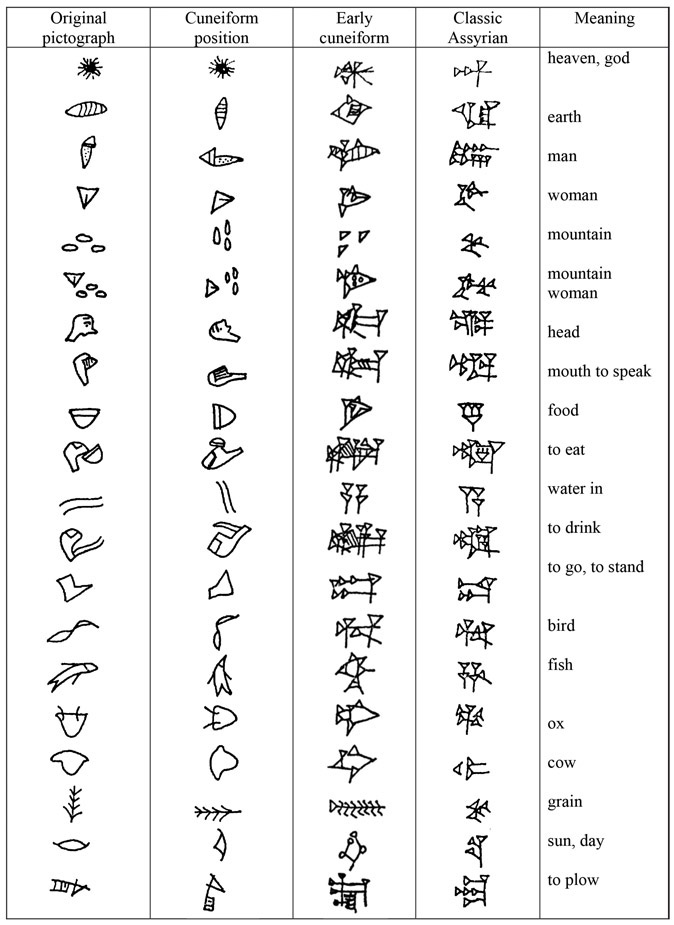

*来源*：Diringer（1962）。

*Source*: Diringer (1962).

他们的优势手打手语。随着手语使用者群体越来越大，这种语言开始变得更加复杂，使用了面部表情和躯干，最终还用非优势手来提供更多的细微差别。而且，第一代手语使用者每分钟大约打104个手势，而最新一代则变得高效得多，每分钟153.2个手势。<sup>9</sup>这种语言随着时间推移变得更加细致、更加高效。一条认知捷径出现了。

their dominant hand. As the community of signers grew larger, the language started to become more complex, with facial expressions and torso, and ultimately the nondominant hand was used to provide more nuances. Moreover, whereas the first generation of signers signed about 104 signs per minute, the latest generation has become far more efficient with 153.2 signs per minute.<sup>9</sup> The language became more nuanced and more efficient over time. A cognitive shortcut emerged.

如果我们不想等八十年来看一种语言如何演变，我们可以模拟语言演变。爱丁堡大学的一个研究团队想出了一个非常巧妙的办法，在实验室里重现语言演变<sup>10</sup>，既不必依赖泥板，甚至也不必依赖一种虽然只用了八十年就演变了的手语。他们通过做一个你小时候可能玩过的游戏来模拟一代代语言使用者：传话游戏，你对旁边的人耳语一句话，她把听到的耳语给她旁边的人，后者又把听到的耳语给她旁边的人，如此等等。最终结果总是很滑稽，因为原来的信息几乎经受不住（耳语的）时间考验。西蒙·柯比和他的团队做了类似的事，让参与者把一句话耳语给下一个人，下一个人再把这句话耳语给下一个人。研究者还录制了一段参与者用哑剧表演一个概念的视频，并把录像给另一名参与者看，后者再向另一名参与者用哑剧表演这个概念——例如用哑剧表演*photographer*（摄影师）这个词。在第一代中，一名参与者会用哑剧表演拿着相机，用右手食指按下相机顶部的按钮，举起手让想象中的人停下，然后把手转个圈仿佛示意想象中的人转身，再用食指按一下想象中的按钮。一场模特拍摄的哑剧。到第五代，哑剧看起来就大不相同了。你看到有人指着自己，用食指做了三个连续的按快门动作。就这样。从这个哑剧中获取意义更难了，因为它短得多，也简单得多。这似乎是一条认知捷径。

If we don’t want to wait eighty years to see how a language evolves, we might simulate language evolution. A team of researchers at the University of Edinburgh came up with a very clever idea to recreate language evolution in the lab,<sup>10</sup> not having to rely on clay tablets, and not even having to rely on a sign language that evolved albeit in only eighty years. They simulated generations of language users by doing the game you might have played when you were younger: the Telephone Game, in which you whisper something to the person next to you, who whispers what she heard to the person next to her, who whispers what she heard to the person next to her, and so on. The end result is always funny, as very little of the original message actually stands the test of (whispering) time. Simon Kirby and his team did something similar, asking participants to whisper an utterance to the next person, who would whisper the utterance to the next person. The researchers also recorded a video of a participant pantomiming a concept and showed the recording to another participant, who would then pantomime the concept to another participant—for instance, the pantomiming of the word *photographer*. In the first generation a participant would pantomime holding a camera, clicking the button on top of the camera with her right index finger, holding up her hand to stop the imagined person, then circling her hand as if to point the imagined person to turn around, and clicking the imagined button with her index finger again. A pantomime of a model shoot. In the fifth generation the pantomime looked very different. There you see somebody pointing at himself, and making three consecutive clicking movements with his index finger. That’s it. It is harder to get the meaning out of the pantomime because it is much shorter and far less complex. It seems to be a cognitive shortcut.

每当我想到苏美尔文字的演变、以色列手语跨代的变化，以及在实验室里模拟语言演变的实验时，我都会想起高中时经济学老师向我解释货币的演变。这个故事与语言的演变很相似。在早期，人们交换他们的货物。如果我有一头牛，我就有牛奶。如果你有谷物，你就有面包。所以我们可以用我的牛奶交换你的面包。产品的价值大致相同，而且这个价值可以直接追溯到我们交换的产品上。然而，随着时间推移，事情变得有点麻烦。如果你不需要牛奶，我仍然得确保在它变质之前把它换掉。而随着交易者群体变大，这就说得通了：我可以把我的牛奶换给别人，他可能有些肉，而肉又可以换成面包。但随着群体越来越大，用某种更抽象一点的东西——比如金或银——来替代具有特定价值的实际产品（面包、牛奶、肉）似乎更容易。我的牛奶现在可以换成一些等值的银子。好处是我可以更高效地交易，并且仍然确信我的产品会保持其价值。然而，随着时间推移，当交易群体对“一个概念保持其价值”这一原则建立起信任时，金或银就可以被某种更抽象的东西替代，比如一张纸。只要每个人都同意这张纸代表我们约定的价值，这张（实际上毫无价值的）纸就值我的牛奶的价值。

Whenever I think of the evolution of Sumerian, the changes across generations in Israeli Sign Language, and the experiments that simulate language evolution in the lab, I get reminded of my economics teacher in high school explaining to me the evolution of money. The story is similar to the evolution of language. In the early days, people traded their goods. If I had a cow, I had milk. If you had grain, you had bread. And so we could trade my milk and your bread. The value of the products was about the same, and that value could be directly linked back to the product we traded. Over time, however, things became a little cumbersome. If you didn’t need milk, I still had to make sure I would trade it before it became spoiled. And with a larger community of traders, that made sense: I could trade my milk to somebody else who may have had some meat, which could be traded in for bread. But with a community growing larger and larger, it seemed easier to replace the actual product with specific value (bread, milk, meat) for something a little more abstract, like gold or silver. My milk could now be traded in for some silver, with the same value. The advantage was that I could trade more efficiently and would still be certain my products would retain their value. Over time, however, as the trading community developed trust in the principle of a concept keeping its value, the gold or silver could be replaced with something even more abstract, for instance, a piece of paper. As long as everybody agreed the piece of paper meant the value we agreed on, that piece of (actually worthless) paper would be worth the value of my milk.

货币与语言之间的比较可能显得牵强，但它说明了一些有趣的相似之处。符号与其意义之间的关系最初基于相似性，随着时间推移变得更加抽象，符号与其意义之间还保留一些相似性，最终变得完全抽象。抽象的过程可以用越来越大的人群接受“符号与其所指之间不存在关系”来解释。只要群体达成一致，符号系统就能运作。它还提供了一条方便的认知捷径，使人不再需要记住所有的形式和意义。

The comparison between money and language may seem farfetched, but it illustrates some interesting similarities. Whereas the relation between the sign and its meaning was initially based on similarity, over time it became more abstract, with some similarity between the sign and its meaning, to ultimately being fully abstract. The process of abstraction can be explained by a growing community of people buying into the absence of a relation between the sign and what it means. As long as the community agreed, the sign system worked. It also provided a convenient cognitive shortcut, so it was no longer necessary to keep in mind all forms and meanings.

## 声音与意义

## SOUNDS AND MEANING

让我们假设一种我们俩都不懂的语言。这种语言有我们不知道意义的词，但幸运的是，有两个词及其意义是已知的。这两个词是*kiki*和*bouba*。两个词的意义一个是尖刺状的形状，另一个是圆鼓鼓的形状。但对我们这些外语学习者来说不幸的是，这两个形状的标签被弄混了，所以我们不确定哪个形状叫*kiki*，哪个叫*bouba*。尖的那个是*bouba*还是*kiki*？圆鼓鼓的那个呢？你会选哪个？

Let’s assume a language neither one of us knows. The language has words we do not know the meaning of, but luckily for us, two words and their meanings are known. The words are *kiki* and *bouba*. The meanings of the two words are a spiky pointy shape and the other a bubbly round shape. But unfortunate for us foreign language learners, the labels of the two shapes have actually been mixed up, so we do not really know which shape is called *kiki* and which one *bouba*. Is the spiky one *bouba* or *kiki*? And what about the bubbly one? Which one would you choose?

在二十世纪早期，德国心理学家沃尔夫冈·苛勒请参与者给不同的形状命名。<sup>11</sup>参与者看到一个星形和一个泼墨形，并被问到哪个最有可能叫*takete*或*buluba*。参与者绝大多数为有尖锐边缘的形状选择了*takete*，为较圆的形状选择了*baluba*。在后来的实验中，*takete*被换成了*kiki*，*buluba*被换成了*maluma*和*bouba*，但结果是一样的。参与者把需要较圆口型的词分配给较圆的形状，把口型较有棱角的词分配给较有棱角的形状。

In the early part of the twentieth century, German psychologist Wolfgang Köhler asked participants to give names to different forms.<sup>11</sup> Participants were presented with a star shape and a spilled-ink shape and were asked which one would be most likely called *takete* or *buluba*. Participants overwhelmingly choose *takete* for the shape with the sharp edges, and *baluba* for the more round shape. In later experiments, *takete* was replaced with *kiki*, and *buluba* with *maluma* and *bouba*, but the outcomes were the same. Participants assigned the word requiring a rounder shape of the mouth to the rounder shapes, and the word with a more angular mouth shape to the more angular shape.

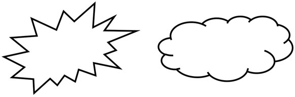

但*kiki-bouba*效应并不局限于以*k*或*b*开头的辅音，也不局限于尖的和圆的形状。这种效应在元音中也能找到。让我们再回到那种我们不会说的编造的语言。在我们编造的语言中发现了新词，我们又一次很幸运，因为我们被告知了这些词的意思。它们指的是较小和较大的格里布（greebles），一种蓝色的小怪物，体型可以像狗、鹿、牛、大象或恐龙那样大，用来表示这些概念的词有*tikiti, tebibi, kekomo, wutoli*和*gobudu*。<sup>12</sup>和*bouba*与*kiki*一样，这些词的标签又被弄混了。我们根本不知道最小的格里布是*gobudu*还是*tikiti*。我们大多数人的猜测非常一致。我们把/*i*/和/*e*/元音留给小格里布，把/*u*/和/*o*/留给最大的格里布。根据我们以及参与者的直觉，*Tikiti, tebibi, kekomo, wutoli*和*gobudu*按大小排得很整齐。而格里布们也同意。<sup>13</sup>

But the *kiki-bouba* effect is not limited to consonants that start with a *k* or *b* or to spiky and round shapes. The effect can also be found for vowels. Let’s go back again to the made-up language that we do not speak. New words have been discovered in our made-up language, and again we are lucky because we are informed what the words mean. They refer to smaller and larger greebles, blueish little monsters that can take the size of a dog, deer, cow, elephant, or dino, concepts with words like *tikiti, tebibi, kekomo, wutoli*, and *gobudu*.<sup>12</sup> As with *bouba* and *kiki*, the labels for these words are mixed up again. We simply do not know whether the smallest greeble is *gobudu* or *tikiti*. For most of us, we guess very homogeneously. We reserve the /*i*/ and /*e*/ vowels for small greebles and /*u*/ and /*o*/ for the largest greebles. *Tikiti, tebibi, kekomo, wutoli*, and *gobudu* are nicely ordered according to size according to our, and the participants’, intuition. And the greebles agree.<sup>13</sup>

也许我们之所以猜较小的格里布是*tikiti*或*tebibi*、较大的格里布是*wutoli*和*gobudu*，是因为与我们确实认识的词的联想：表示小的词如*little*、*tiny*、*mini*、*bit*、*dinky*、*micro*、*slim*和*lesser*；表示大的词如*large*、*tall*、*bold*、*ample*、*bulky*、*grand*、*macro*、*massive*、*monstrous*、*super*和*voluminous*。当然，这本身就很有意思。也许作为英语使用者，我们遵循自己语言的模式，并把它们应用到我们不懂的语言上。但这告诉我们的也许更多是关于我们懂的语言，而不是我们不懂的语言。而且，在小和大之间作决定似乎相当二元。我们不认识的那个词要么更大，要么更小。就这样。如果我们请人们就这些词在大和小之外的多个特征上给出意义呢？

Perhaps we guessed smaller greebles to be *tikiti* or *tebibi*, and larger greebles to be *wutoli* and *gobudu*, because of the associations with words that we do know: smaller words such as *little*, *tiny*, *mini*, *bit*, *dinky*, *micro*, *slim*, and *lesser*; and larger words such as *large*, *tall*, *bold*, *ample*, *bulky*, *grand*, *macro*, *massive*, *monstrous*, *super*, and *voluminous*. Of course, that is interesting in itself. Perhaps as English language users we follow the patterns of our language and apply them to the language we do not know. But it may tell us more about the language that we do know than the language that we do not. Moreover, the decision between small and large seems rather binary. The word we do not know is either larger or smaller. That’s it. What if we asked people for the meaning of these words on multiple features, beyond large and small?

在另一项巧妙的研究中<sup>14</sup>，研究者给参与者两打不存在的词，比如*ackie*、*ambous*、*axittic*、*bomburg*、*cougzer*、*gricker*、*flissil*、*keex*、*heonia*、*cruckwic*、*horgous*和*boodoma*。有了足够多这样的不存在的词，我们就能构建一种全新的语言！参与者被问到这些词中的每一个最适合用以下哪些特征来描述：支配的、小的、大的、尖的、女性化的、聪明的、圆的、顺从的、不聪明的或男性化的。他们可以选择一到四个特征来描述这些不存在的词。但他们还没完。

In another clever study,<sup>14</sup> two dozen nonexisting words were given to participants, such as *ackie*, *ambous*, *axittic*, *bomburg*, *cougzer*, *gricker*, *flissil*, *keex*, *heonia*, *cruckwic*, *horgous*, and *boodoma*. With enough of these nonexisting words, we can build an entirely new language! Participants were asked whether each of these words was best described as being dominant, small, large, spiky, feminine, intelligent, round, submissive, unintelligent, or masculine. They could choose one to four features describing the nonexisting words. But they were not done yet.

接下来，他们被要求画出一个看起来像这个不存在的词的生物。例如，一个*horgous*会是什么样子？很酷的是——在书呆子的意义上——我们现在知道了三件事：这个词（*horgous*）、特征（例如它是大的和男性化的），以及对*horgous*长什么样的一种解释。更酷的是——在更书呆子的意义上——我们现在可以请另一组参与者给出别人画的生物的名字（它是*horgous*、*bomburg*还是*fissil*？）以及与这幅画相符的特征（它是支配的、小的、大的、尖的、女性化的、聪明的、圆的、顺从的、不聪明的还是男性化的？）。而最酷的是——在最书呆子的意义上——结果完全一致。参与者认为一幅*horgous*的画是大的和圆的，完全符合其他参与者赋予*horgous*这个词的特征。一幅*keex*的画被认为是小的和尖的，正如其他参与者赋予*keex*这个词的特征。根据两组不同的参与者赋予画和词的特征，*Heonia*被认为是女性化的。而当参与者搞混了、没能为那幅大而男性化的怪物画说出*horgous*这个词时，他们更可能把它与*bomburg*混淆，而不是与*keex*混淆。多酷啊？

Next, they were asked to draw a creature that looked like the nonexisting word. For instance, what would a *horgous* look like? What is cool—in a nerdy sense—is that we now know three things: the word (*horgous*), the features (e.g., that it is large and masculine), and an interpretation of what a *horgous* looks like. What is even cooler—in an even nerdier sense—is that we can now ask another group of participants to give the name of the creature somebody else drew (is it a *horgous*, a *bomburg*, or a *fissil*) and the features that go with the drawing (is it dominant, small, large, spiky, feminine, intelligent, round, submissive, unintelligent, or masculine?). And what is coolest—in the nerdiest sense—is that the results were fully consistent. The picture of a *horgous* was considered by participants to be large and round, fully in line with the features other participants gave to the word *horgous*. A picture of a *keex* was considered to be small and spiky, just like the features given to the word *keex* by other participants. *Heonia* was considered feminine, according to the features given to the picture and the features given to the word, by two different groups of participants. And when participants got confused, and did not get the word *horgous* right for the large masculine drawing of a monster, they were more likely to confuse it with a *bomburg* than with a *keex*. How cool is that?

当然，我们可以认为，这些声音–意义效应是在一个无意义词与一个选定特征之间习得映射的结果。通过反复展示这个词和一个选定的意义，就很容易把特定的无意义词与特定的特征联系起来。而且，参与者有机会仔细地自我斟酌，找出哪个词的特征最符合哪个意义特征。你也许会这么想。但事实并非如此。圆的声音与圆的物体、尖的声音与尖的物体之间的映射，不仅在成年人身上能找到，在小至2.5岁的儿童身上也能找到。<sup>15</sup>那么，在你把*shick*与尖的物体、把*dom*与圆的物体联系起来之前的仔细斟酌呢？脑成像研究表明，这种映射早在你看到尖的或圆的物体图片后140–180毫秒就发生了。<sup>16</sup>这根本不够任何斟酌，但对于一条认知捷径来说已经够快了。

Of course, we could argue that these sound–meaning effects are found as a consequence of learned mapping between a nonsense word and a selected feature. By repeatedly showing the word and a selected meaning, it becomes easy to link specific nonsense words to specific features. Moreover, participants had the opportunity to go into a careful deliberation with themselves to find out which word feature best fits which meaning feature. That’s what you may think. And that is not actually the case. The mapping between rounded sounds and rounded objects and spiky sounds with spiky objects is found not only in adults but also in children as young as 2.5 years old.<sup>15</sup> And what about the careful deliberation before you link *shick* to the spiky object and *dom* to the rounded object? Brain-imaging studies show that this mapping happens as early as 140–180 milliseconds after you see the picture of the spiky or rounded object.<sup>16</sup> Not enough at all for any deliberation, but fast enough for a cognitive shortcut.

这些例子表明，一个词的声音中有一些线索可能会透露其意义的某些方面。如果我们看看实际的语言样本，有相当多的例子表明，一个词的声音与其意义之间那种假定的任意关系不应像本章开头所暗示的那样被轻易否定。例如：

These examples show that there are cues in the sound of the word that may give away aspects of its meaning. If we look at actual language samples, there are quite a few examples that demonstrate that the presumed arbitrary relation between the sound of a word and its meaning should not be so readily dismissed as the beginning of this chapter suggested. For instance:

- *clank*、*clash*、*clap*、*clack*、*cling*、*click*、*cluck*、*clamp*、*clip*、*clod*、*clog*、*clam*、*clinch*、*clutch*、*clasp*、*clump*、*clench*、*claw*、*clay*和*cloy*暗示着一种铿锵声（clang）；  
  *clank*, *clash*, *clap*, *clack*, *cling*, *click*, *cluck*, *clamp*, *clip*, *clod*, *clog*, *clam*, *clinch*, *clutch*, *clasp*, *clump*, *clench*, *claw*, *clay*, and *cloy* suggest a clang;
- *float*、*flush*、*flee*、*flail*、*flop*、*flap*、*fleet*、*flit*、*flag*、*flex*、*fling*、*flare*、*flash*、*flip*、*flick*、*flat*、*flaunt*、*fluster*、*fleck*、*flirt*、*flinch*和*flake*暗示着一种流动（flow）；  
  *float*, *flush*, *flee*, *flail*, *flop*, *flap*, *fleet*, *flit*, *flag*, *flex*, *fling*, *flare*, *flash*, *flip*, *flick*, *flat*, *flaunt*, *fluster*, *fleck*, *flirt*, *flinch*, and *flake* suggest a flow;
- *glint*、*gloss*、*glare*、*glaze*、*glee*、*glad*、*glimpse*、*glance*、*gloom*、*gloat*、*glum*、*glide*、*globe*和*glove*暗示着一种光亮（glow）；  
  *glint*, *gloss*, *glare*, *glaze*, *glee*, *glad*, *glimpse*, *glance*, *gloom*, *gloat*, *glum*, *glide*, *globe*, and *glove* suggest a glow;
- *skid*、*skip*、*skate*、*skimp*、*scud*、*scour*、*skirt*、*scope*、*skin*、*sketch*、*skew*、*scat*、*scoff*、*scare*和*skull*暗示着掠过（skimming）；  
  *skid*, *skip*, *skate*, *skimp*, *scud*, *scour*, *skirt*, *scope*, *skin*, *sketch*, *skew*, *scat*, *scoff*, *scare*, and *skull* suggest skimming;
- *stick*、*stump*、*stanch*、*steep*、*stall*、*stuff*、*stir*、*stamp*、*sting*、*stomp*、*stash*暗示着僵硬（stiffness）；  
  *stick*, *stump*, *stanch*, *steep*, *stall*, *stuff*, *stir*, *stamp*, *sting*, *stomp*, *stash* suggest stiffness;
- *stripe*、*strip*、*stretch*、*streak*、*strait*、*string*、*strap*、*stream*、*stride*、*strive*、*strut*、*strum*、*strength*、*strain*、*stroll*、*strife*、*strange*、*strew*、*stress*暗示着某种直的东西（straight）；  
  *stripe*, *strip*, *stretch*, *streak*, *strait*, *string*, *strap*, *stream*, *stride*, *strive*, *strut*, *strum*, *strength*, *strain*, *stroll*, *strife*, *strange*, *strew*, *stress* suggest something being straight;
- *swish*、*swoop*、*swipe*、*sweep*、*swirl*、*swat*、*swoon*、*switch*、*swag*、*swap*、*swell*、*swill*和*swim*暗示着某种摆动的东西（swinging）；  
  *swish*, *swoop*, *swipe*, *sweep*, *swirl*, *swat*, *swoon*, *switch*, *swag*, *swap*, *swell*, *swill*, and *swim* suggest something swinging;
- *creep*、*crack*、*crick*、*cramp*、*crutch*、*creak*、*crouch*、*cross*、*cringe*、*crane*、*croak*、*crimp*、*crag*、*crow*、*crash*、*crawl*、*crunch*、*crush*、*crib*、*crate*、*crump*、*crab*、*crumb*暗示着某种弯曲的东西（crooked）；  
  *creep*, *crack*, *crick*, *cramp*, *crutch*, *creak*, *crouch*, *cross*, *cringe*, *crane*, *croak*, *crimp*, *crag*, *crow*, *crash*, *crawl*, *crunch*, *crush*, *crib*, *crate*, *crump*, *crab*, *crumb* suggest something being crooked;
- *drift*、*droop*、*drape*、*drawl*、*drown*、*dregs*、*drug*、*drain*、*droll*、*drench*、*drool*、*drip*、*dry*、*drum*、*dram*都拖拖拉拉（drag on）；  
  *drift*, *droop*, *drape*, *drawl*, *drown*, *dregs*, *drug*, *drain*, *droll*, *drench*, *drool*, *drip*, *dry*, *drum*, *dram* all drag on;
- *grunt*、*groan*、*gruff*、*grim*、*grouse*、*grudge*、*grasp*、*grope*、*grab*、*grip*、*graft*都在低吼（growl）；  
  *grunt*, *groan*, *gruff*, *grim*, *grouse*, *grudge*, *grasp*, *grope*, *grab*, *grip*, *graft* all growl;
- *slip*、*slope*、*slant*、*slick*、*slink*、*sleek*、*slime*、*sleet*、*sludge*、*slosh*、*slop*、*slouch*、*slough*、*slash*、*slow*、*sling*、*slack*、*slam*、*slay*、*slit*、*sloth*、*slap*、*slog*、*slave*、*slang*都在滑行（slide along）；  
  *slip*, *slope*, *slant*, *slick*, *slink*, *sleek*, *slime*, *sleet*, *sludge*, *slosh*, *slop*, *slouch*, *slough*, *slash*, *slow*, *sling*, *slack*, *slam*, *slay*, *slit*, *sloth*, *slap*, *slog*, *slave*, *slang* all slide along;
- *sniff*、*snort*、*sneeze*、*snore*、*snuff*、*snarl*、*sneer*、*snoop*、*snub*、*snob*、*snack*、*snap*、*sneak*、*snatch*、*snag*、*snip*都与口鼻（snout）有关；  
  *sniff*, *snort*, *sneeze*, *snore*, *snuff*, *snarl*, *sneer*, *snoop*, *snub*, *snob*, *snack*, *snap*, *sneak*, *snatch*, *snag*, *snip* all have something to do with a snout;
- *squash*、*squirt*、*squirm*、*squelch*、*squeal*、*squeak*、*squawk*、*squid*、*squall*、*squander*相互挤压（squeeze）。<sup>17</sup>  
  *squash*, *squirt*, *squirm*, *squelch*, *squeal*, *squeak*, *squawk*, *squid*, *squall*, *squander* squeeze each other out.<sup>17</sup>

这些词开头的声音透露了它们意义的特征。如果我向你呈现*glim*这个词，你可能完全不知道这个十七世纪的古词是什么意思，但听到它指的是提供光亮的东西（比如灯笼或蜡烛），你不会很惊讶；同样，*slugabed*——另一个十七世纪的古词——指的是沙发土豆，即在床上躺得太久的人。

The sounds at the beginning of these words give away features of their meaning. If I presented you with the word *glim*, you may have absolutely no idea what this archaic seventeenth-century word means, but you would not be very surprised to hear it means something that furnishes light (like a lantern or candle), or that a *slugabed*, another seventeenth-century archaic word, is a couch potato, a person who stays in bed for too long.

你说得对，这些都是精心挑选、用来证明我观点的词。这些例子的问题在于，它们仅仅是例子而已。每个类别有二十到三十个词符合该类别，而以*cl*-、*cr*-或*sl*-音开头的很多词——*clown*（小丑）、*cradle*（摇篮）和*slot*（槽）——并不完全符合。而如果在我们认识的六万个词中，每个类别有大约二十个词符合——尽管这似乎相当不可能，因为那样上面呈现的列表本应长得多——我们仍然得记住两千个类别。而且，它们是从精心挑选的类别中精心挑选出来的词。它们如何在一种语言中推广开来？

And you are right, these are carefully cherry-picked words that prove my point. The problem with these examples is that they are just that: examples. For each category there are twenty to thirty words that fit the category, while there are many words starting with a *cl*-, *cr*-, or *sl*- sound—*clown*, *cradle*, and *slot*—that do not quite fit the bill. And if for the sixty thousand words we know, there are some twenty words that fit each category—though this seems to be rather unlikely, as the list presented above should then have been considerably longer—we would still have to remember two thousand categories. Moreover, they are carefully selected words from carefully selected categories. How do they generalize across a language?

语料库语言学研究也许能来救场。可以对大量的词按其声音进行分析，并描绘出具有这些声音的词的数量与某一特定词类之间的关系。例如，我们可以取大量的词，看看这些词的声音如何让我们区分我们处理的是名词还是动词。大量研究表明，仅凭一个词的声音（而不是其形态），就有可能以超过90%的准确率预测它是名词还是动词。<sup>18</sup>这意味着，一个词是不是一个活动<sup>19</sup>，仅凭其声音就可以确定，不仅对英语如此，对荷兰语、德语和日语也是如此，而且不是对少数几个词，而是对成千上万个词！这意味着语言使用者可以利用一个词的声音来识别他们处理的是名词还是动词，这不仅意味着他们可以估计自己处理的是一个活动（动词）还是一个概念（名词），还意味着他们可以对句子的结构作出估计——不仅基于句法规则或词的意义，也基于词的声音。这些不只是语料库语言学或计算语言学的观察。语言使用者在在线句子加工中会使用这些信息。以下面两个句子为例<sup>20</sup>：

Corpus linguistic studies may come to the rescue. Large numbers of words can be analyzed on their sounds, and the relationship between the number of words that have these sounds and a particular word category can be mapped out. For instance, we could take a large number of words and see how the sounds of these words allow for distinguishing whether we are dealing with nouns or verbs. Extensive studies have shown that it is possible with over 90 percent accuracy to predict whether a word is a noun or a verb, solely on the basis of its sound (and not its morphology).<sup>18</sup> That means that knowing whether a word is an activity<sup>19</sup> or not can be established only on the basis of its sound, not just for English, but also for Dutch, German, and Japanese, and not for a few words, but for thousands of words! This means that language users can use the sound of the word to identify whether they are dealing with a noun or a verb, which means not only that they can make estimates about whether they are dealing with an activity (verb) or a concept (noun), but also that they can make estimates about the structure of the sentence—not only on the syntactic rules or the meaning of the word but also on the basis of the sound of the word. These are not corpus linguistic or computational linguistic observations. Language users use this information in online sentence processing. Take for instance the two sentences below<sup>20</sup>:

> Chris and Ben are glad that the bird perches seem easy to install.（克里斯和本很高兴这些鸟栖木看起来很容易安装。）

> Chris and Ben are glad that the bird perches seem easy to install.

> Chris and Ben are glad that the bird perches comfortably in the cage.（克里斯和本很高兴那只鸟舒服地栖息在笼子里。）

> Chris and Ben are glad that the bird perches comfortably in the cage.

两个句子都包含*perches*这个词，这是一个同形同音异义词。它可以指鸟可以栖息的栖木，即一根树枝或横杆；也可以指栖息的过程，即在树枝上休息。所以这个词可以是名词也可以是动词，是一个概念也可以是一个活动。仅凭这个词本身，没有任何东西告诉我们它是哪一个。然而，对这个词声音的广泛分析表明，从声音上看，*perch*更像名词而不是动词。

The two sentences both include the word *perches*, a word that is a homonym. It can mean a perch a bird can rest on, a branch or horizontal bar, or the process of perching, the resting on the branch. The word can thus be a noun or a verb, a concept or an activity. Based on the word itself, there is nothing that tells us whether it is one or the other. An extensive analysis of the sound of the word, however, showed that on the basis of the sound, *perch* is noun-like than more verb-like.

当参与者被要求阅读这样的句子时，他们读第一个句子直到*perches*这个词的速度更快——尽管他们还没有看到句子的其余部分。像*needs*这样的词也有两个意义：需要帮助的状态，即必需品；*或者*需要帮助的过程，如下所示——名词或动词，概念或活动。

And when participants were asked to read sentences like these, they read the first sentence until the word *perches* faster—even though they had not yet seen the rest of the sentence. A word like *needs* also has two meanings: the state of requiring help, the necessity, *or* the process of requiring help, as below—noun or verb, concept or activity.

> The teacher told the principal that the student needs were not being met.（老师告诉校长，学生的需求没有得到满足。）

> The teacher told the principal that the student needs were not being met.

> The teacher told the principal that the student needs to be more focused.（老师告诉校长，这个学生需要更专注。）

> The teacher told the principal that the student needs to be more focused.

一项语料库语言学分析发现，*needs*更像动词而不是名词。当参与者阅读这些句子时，他们读第二个句子比读第一个句子要快得多。所以，尽管看起来词的声音与其意义之间是任意的关系，但也有例外，即那些符合铿锵、流动、粘连、摆动和漂移倾向的词。尽管这些词可能是精心挑选的，但这种模式对于与格里布大小或horgous性质相关的无意义词同样成立。而对于整个语言来说，一个词的声音似乎能够可靠地（但并非完美地）区分这个词是名词还是动词，或者它在效价上更正面还是更负面。阅读和反应时研究证实，语言使用者在阅读和理解过程中会利用这些模式。

A corpus linguistic analysis found that *needs* is more a verb than a noun. When participants read these sentences, they were considerably faster in the second than in the first sentence. So even though it may seem that the sounds of words have an arbitrary relationship with their meaning, there are exceptions with words that fit a clanging, flowing, sticking, swinging, and drifting tendency. Though these words may be carefully chosen, the pattern holds up for nonsense words that relate to the size of greebles or the nature of a horgous. And for language at large, it seems that the sound of a word can distinguish reliably (but not perfectly) whether the word is a noun or a verb, or whether it is more positive or negative in valence. Reading and response time studies confirm that language users employ these patterns in their reading and comprehension processes.

在另一项很酷的研究中——这样的研究有很多——参与者被要求首先对词的象似性进行评分。<sup>21</sup>他们得到的说明大致如下：

In another cool study—there are many of them—participants were asked to first rate words on their iconicity.<sup>21</sup> They got an instruction like the following:

> 有些英语单词听起来就像它们的意思。例如，SLURP（啜饮）听起来就像你做这种喝水动作时发出的声音。一个与动作声音无关的例子是TEENY（极小的），它听起来像某种非常小的东西（与听起来很大的HUGE相比）。这些词是象似的。即使你不懂英语，你也可能猜出这些词的意义。词也可以听起来与它们的意思相反。例如，MICROORGANISM（微生物）是一个表示非常小的东西的大词。而WHALE（鲸）是一个表示非常大的东西的小词。最后，许多词既不是象似的，也不是相反的。例如，DOG（狗）或CAT（猫）这两个词听起来没有任何犬类或猫科的味道。这些词是任意的。如果你不懂英语，你就无法猜出这些词的意义。<sup>22</sup>

> Some English words sound like what they mean. For example, SLURP sounds like the noise made when you perform this kind of drinking action. An example that does not relate to the sound of an action is TEENY, which sounds like something very small (compared to HUGE which sounds big). These words are iconic. You might be able to guess these words’ meanings even if you did not know English. Words can also sound like the opposite of what they mean. For example, MICROORGANISM is a large word that means something very small. And WHALE is a small word that means something very large. And finally, many words are not iconic or opposite at all. For example there is nothing canine or feline sounding about the words DOG or CAT. These words are arbitrary. If you did not know English, you would not be able to guess the meanings of these words.<sup>22</sup>

研究者由此得以获得大约三千个词的象似性评分。参与者觉得*humming*（嗡嗡声）、*click*（咔嗒声）和*hissing*（嘶嘶声）这些词非常象似。词的声音透露了它的意义。但按照参与者的说法，像*dandelion*（蒲公英）、*silent*（安静的）和*would*这样的词则不然。除了拟声词之外，动词、形容词和副词总体上被认为是象似的，但名词不太是。这些词还按所描述的模态进行了划分。视觉词如*murky*（昏暗的）、*tiny*（极小的）和*quick*（快的）；味觉词如*juicy*（多汁的）、*suck*（吮吸）和*chewy*（有嚼劲的）；以及嗅觉词如*sniff*（嗅）和*whiff*（一股气味）都是象似的。触觉词如*mushy*（糊状的）、*crash*（碰撞）和*crisp*（脆的），以及听觉词如*hissing*、*buzzing*（嗡嗡声）和*clank*（叮当声）也是象似的。然而总体而言，视觉词、味觉词和嗅觉词的象似性得分低于听觉词和触觉词。所以在大约三千个词中发现了象似性，但象似性水平因句法范畴或这些词可以关联的模态而有所不同。

The researchers were then able to have iconicity ratings for some three thousand words. Participants felt that the words *humming*, *click*, and *hissing* were very iconic. The sound of the word gave away its meaning. But words like *dandelion*, *silent*, and *would* did not, according to the participants. In addition to onomatopoeias, verbs, adjectives, and adverbs were overall considered iconic, but nouns were not so much. The words were also split up by the modality they were describing. Visual words like *murky*, *tiny*, and *quick*; gustatory words like *juicy*, *suck*, and *chewy*; and olfactory words like *sniff* and *whiff* were iconic. And tactile words like *mushy*, *crash*, and *crisp*; and auditory words like *hissing*, *buzzing*, and *clank* were also iconic. Overall, however, the iconicity scores for visual, gustatory, and olfactory words were lower than those for auditory and tactile words. So across some three thousand words, iconicity was found, but the level of iconicity by syntactic category or the modality the words could be linked to varied.

在我自己的实验室里，我们研究了这样一个问题：我们能否识别出可能为语言使用者提示一个词的意义的声音。<sup>23</sup>我们取了成千上万个参与者已经评定为较正面或较负面的词。像*torture*（折磨）、*murder*（谋杀）和*morgue*（停尸房）这样的词在负面效价上最为突出，而*birthday*（生日）、*vacation*（假期）和*happiness*（幸福）在正面效价上最为突出。对于所有这数千个词，我们识别出了所有的音位，即一个词的声音。然后我们计算这个词是否以塞音（如*t*、*k*、*p*或*d*、*g*、*b*）开头，或者塞音是否出现在词中间的某个地方，以及出现了多少次。我们计算了元音的数量以及它们在词中出现的位置，对鼻音（如*n*和*m*）也做了同样的计算。大约二十种声音特征被编码，不仅针对英语，也针对荷兰语和德语。在我们的工作中，我们还加入了汉语。我们的任务是确定能最大限度区分正面效价和负面效价的最少音位数。<sup>24</sup>而对于我们研究的所有四种语言，一个音位就造成了差异。如果一个词以鼻音开头，它就能告诉我们一点关于这个词效价的信息。不多，但刚好够。

In my own lab, we investigated the question of whether we could identify sounds that might cue language users on the meaning of a word.<sup>23</sup> We took thousands of words that participants had already rated as being more positive or more negative. Words like *torture*, *murder*, and *morgue* excelled in negative valence and *birthday*, *vacation*, and *happiness* in positive valence. For all these thousands of words, we identified all the phonemes, the sounds of a word. We then computed whether the word started with a plosive (like *t*, *k*, *p* or *d*, *g*, *b*) or whether the plosive occurred somewhere in the middle of the word, and how often. We computed the number of vowels and where they occurred in the word, as we did with nasals (like *n* and *m*). Some twenty sounds characteristics were coded, not just for the English language, but also for Dutch and German. And in our efforts, we added Chinese. Our task was to determine the smallest number of phonemes that would maximally distinguish between positive and negative valence.<sup>24</sup> And for all four languages we looked at, one phoneme made the difference. If a word started with a nasal, it told us a little bit about the valence of a word. Not a lot, but just enough.

更有意思的是，在英语、荷兰语和德语中，词首的鼻音告诉我们这个词的意义更负面，但在汉语中，当一个词以鼻音开头时，它被认为意义更正面。这使我们得以进行几项实验。在第一项实验中，我们向荷兰参与者呈现中性效价的荷兰语词，向中国参与者呈现中性效价的汉语词，比如*lipstick*（口红）、*speculation*（推测）、*reaction*（反应），以及*noun*（名词）、*notification*（通知）和*north*（北方）。这些词在意义上既不正面也不负面，只有一半以鼻音开头。荷兰参与者认为以鼻音开头的中性效价词更负面；中国参与者则正好相反。然后我们把以鼻音开头和不以鼻音开头的汉语词分开，把汉语词呈现给一句汉语都不会说的荷兰参与者，把荷兰语词呈现给一句荷兰语都不会说的中国参与者。荷兰参与者觉得，他们不认识的外语词以鼻音开头时比不以鼻音开头时听起来更负面。对中国参与者来说，荷兰语词以鼻音开头时听起来更正面。我们把词呈现在屏幕上，也通过耳机播放这些词，结果都是一样的。

Even more interesting, the nasal at the beginning of a word told us that the word was more negative in meaning for English, Dutch, and German, but when a word started with a nasal in Chinese, it was considered more positive in meaning. And this allowed us to conduct several experiments. In the first experiment we presented Dutch words with neutral valence to Dutch participants and Chinese words with neutral valence to Chinese participants, words such as *lipstick*, *speculation*, *reaction*, and *noun*, *notification*, and *north*. These words were neither positive nor negative in meaning, and only half began with a nasal sound. The Dutch participants responded that the neutral-valence words were more negative when they started with a nasal; the Chinese participants did just the opposite. We then divided the Chinese words that started with a nasal and those that did not and presented the Dutch participants who did not speak a word of Chinese with the Chinese words and the Chinese participants who did not speak a word of Dutch with the Dutch words. Dutch participants felt that the foreign words they did not know sounded more negative when they started with a nasal than when they did not. For the Chinese participants, Dutch words sounded more positive when they started with a nasal. We presented the words on a screen, and we presented the words through headphones, and the results were the same.

在效价的例子中，一个词的声音——词首位置的鼻音——为我们提供了一些线索，提示这个词的意义更可能是正面的还是负面的。它做不到完美的准确，但它的模式能使55–60%的词被归入正确的类别，刚好高于偶然水平，而且——对参与者来说——显然刚好足以识别出一个模式——一个能为语言使用者提供认知捷径的模式。

In the case of valence, the sound of a word—the nasal in the first position of the word—gives us some cues on whether the word is more likely to be positive or negative in meaning. It does this not with a perfect accuracy, but its patterns allow for a 55–60 percent classification in the right category, just above chance and—for participants—apparently just enough to recognize a pattern—one that would provide a cognitive shortcut to the language user.

另一项研究<sup>25</sup>采取了相反的方法。这项研究不是在少数几种语言中考察大量的词，而是在大量语言中考察少数几个词。事实上，这项研究考察了数量非常庞大的语言，全世界4,298种语言！在这数千种语言中比较了四十个词在声音上的系统性。其中三十个词，即75%，表现出声音–意义的关联偏向。例如，“小”的意义与高元音/i/相关，比如法语的*petit*、芬兰语的*pieni*、豪萨语的*karami*或匈牙利语的*kicsi*。“圆”的意义在大量语言中与*r*音相关，比如法语（*ronde*）、芬兰语（*pyöristää*）、豪萨语（*da’ira*）或匈牙利语（*kerek*）。“舌头”的意义与/*l*/音相关，“鼻子”与/*n*/音相关，“乳房”与/*m*/音相关。这里声音与意义之间的相似性不能归因于来自同一语系的语言。例如，就语系关系而言，英语与弗里斯兰语、荷兰语和德语最接近，所以这些语言之间有共同之处也许并不奇怪。但在法语、芬兰语、豪萨语和匈牙利语之间发现相似之处就不那么容易解释了。再把这一点扩展到在这些语言中都能找到的四十个词共享相同声音的数千种语言！

Another study<sup>25</sup> took the opposite approach. Rather than looking at a large number of words in a small number of languages, this study looked at a small number of words across a large number of languages. In fact, the study looked at a very large number of languages, 4,298 languages across the world! The systematicity in the sounds of forty words were compared across those thousands of languages. Thirty of these words, or 75 percent, showed a sound–meaning association bias. For instance, the meaning of “small” was associated with a high /i/ sound, as in the French *petit*, Finnish *pieni*, Hausa *karami*, or Hungarian *kicsi*. The meaning of “round” was associated with the *r* sound across a large number of languages, such as French (*ronde*), Finnish (*pyöristää*), Hausa (*da’ira*), or Hungarian (*kerek*). The meaning of “tongue” was linked to an /*l*/ sound, “nose” with an /*n*/ sound, and “breasts” with an /*m*/ sound. The similarities here between sound and meaning could not be attributed to a language coming from the same language family. For instance, English comes closest to Frisian, Dutch, and German in terms of language family relations, so it may be no surprise that there are commonalities across these languages. But finding similarities between French, Finnish, Hausa, and Hungarian is not that easy to explain. And extend that to thousands of languages that share the same sounds for forty words that can be found across these languages!

许多研究表明，我们不能得出结论说一个词的声音与其意义之间的关系是固定的，但仅凭声音来捕捉一个词意义的某些方面是有系统性的。柏拉图大约2,300年前开启的赫莫根尼与克拉底鲁之间的讨论仍在继续。德·索绪尔的格言——支持赫莫根尼阵营——统治了将近一个世纪，而越来越多的研究者拿出了一些令人信服的克拉底鲁式论据，这种论据也许能帮助我们理解我们如何把那些词记在心里，声音–意义模式提供了一条方便的认知捷径。

A number of studies show that we cannot conclude that the relationship between the sound of the word and its meaning is fixed, but that there is systematicity in capturing aspects of the meaning of a word by its sound alone. The discussion between Hermogenes and Cratylus that Plato started some 2,300 years ago continues. With de Saussure’s adage—which supports the Hermogenes camp—reigning for almost a century, there is an increasing number of researchers who bring some convincing Cratylus arguments to the table, an argument that might help us in understanding how we keep those words in mind, with sound–meaning patterns providing a convenient cognitive shortcut.

## 为什么如此任意？

## WHY SO ARBITRARY?

如果有证据表明语言中存在声音–意义关系，那么为什么对于大多数词和大多数类别来说，并不存在这样直接的关系呢？早期的苏美尔象形符号帮助我们识别它们的意义。那么为什么文字系统从形式与意义之间关系不那么清楚的楔形文字，变成了形式与意义之间关系完全缺失的古典亚述文字？为什么形式与意义之间的关系变得任意了？即使计算研究和心理学研究找到了越来越多声音–意义拼图的碎片，越来越多的类别可以用词的声音来解释，但不同语言中声音不同的词表示同样的东西，这一事实仍然存在。语言的演变哪里出了问题？

If there is evidence of a sound–meaning relationship in language, why then is it the case that for most words and most categories, there is no such direct relationship? Early Sumerian pictographs help us identify their meaning. Why, then, did the writing system change from cuneiforms, in which the relationship between form and meaning is less clear, to classic Assyrian script, in which the relationship between form and meaning is absent? Why did the relationship between form and meaning become arbitrary? Even if computational and psychological research find more and more pieces of the sound-meaning puzzle, with more and more categories being explained by the sound of the word, then it is still the case that words with different sounds in different languages mean the same thing. What went wrong in the evolution of language?

想象一个每个词都与其意义有直接关系的世界，比如苏美尔人的世界。泥板上的每个符号都与该符号的意义有直接关系。或者让我们考虑以色列手语的早期几代使用者：每个手势都很好地表示了它的意义。符号与其所指之间的固定关系使理解一个符号变得相当容易，即使对一个不熟悉这种手语的人来说也是如此。学习会相当容易，记忆也不会太复杂。确实，形式与其意义之间的直接关系对于相对少量的符号效果很好，就像最左边那张图所呈现的那样。<sup>26</sup>让我们在横轴和纵轴上画出词与其意义之间的完美关系。在形式轴上的位置与在意义轴上的相同位置完全相关。形式轴上某个位置的头部象形符号直接与意义轴上“头”的意义相连，苏美尔泥板上的*ox*（牛）、*cow*（母牛）、*fish*（鱼）和*grain*（谷物）也是如此。或者以现代英语中的拟声词为例，比如形式轴上的*meow*（喵）、*woof*（汪）、*neigh*（嘶）、*baa*（咩）和*moo*（哞），以及它们在意义轴上各自对应的动物叫声的位置。

Imagine a world in which every word has a direct relation to its meaning, for instance the Sumerian world. Every sign on the clay tablet had a direct relationship with the meaning of that sign. Or let’s consider the early generations of those using Israeli Sign Language: each sign nicely represented what it meant. The fixed relation between the sign and what it means makes it quite easy to understand a sign, even for somebody unfamiliar with the sign language. Learning would be quite easy, and memory would not be too complex. Indeed, the direct relationship between the form and its meaning would work quite well for a relatively small number of signs, as presented in the picture on the far left.<sup>26</sup> Let’s plot the perfect relationship between the word and its meaning on a horizontal and vertical axis. The position on the form-axis perfectly correlates to the same position on the meaning-axis. The pictograph of a head on a position on the form-axis directly links to the meaning of “head” on the meaning-axis, and the same is true for *ox*, *cow*, *fish*, and *grain* on the Sumerian clay tablets. Or take a modern English example of onomatopoeias like *meow*, *woof*, *neigh*, *baa*, and *moo* on the form-axis and their respective position for the animal sound on the meaning-axis.

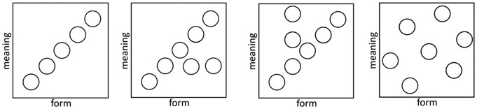

**从象似和固定（左）到任意和随机（右）。*来源*：Gasser（2004）。**

**From iconic and fixed (left), to arbitrary and random (right). *Source*: Gasser (2004).**

但现在让我们增加词形的数量，同时保持认知空间不变，就像左边第二张图那样。更多不同的词形——因为形式轴上有不同的圆圈——表示同一个意思。同义现象进入了系统。词形*gaze*、*see*、*glance*、*watch*、*survey*、*study*、*seek*、*search for*、*peek*、*peep*、*glimpse*、*stare*、*contemplate*、*examine*、*gape*、*ogle*、*scrutinize*、*inspect*、*leer*、*behold*、*observe*、*view*、*witness*、*perceive*、*spy*、*sight*、*discover*、*notice*、*recognize*、*peer*、*eye*、*gawk*、*peruse*和*explore*，仅举几例，都试图留在形式轴上，与“看”这一意义相关联（形式轴上的许多圆圈都在意义轴上有相同的位置）。

But now let’s increase the number of word forms, keeping the cognitive space the same, as in the second picture from the left. More different word forms—because of the different circles on the form-axis—mean the same thing. Synonymy enters the system. The word forms *gaze*, *see*, *glance*, *watch*, *survey*, *study*, *seek*, *search for*, *peek*, *peep*, *glimpse*, *stare*, *contemplate*, *examine*, *gape*, *ogle*, *scrutinize*, *inspect*, *leer*, *behold*, *observe*, *view*, *witness*, *perceive*, *spy*, *sight*, *discover*, *notice*, *recognize*, *peer*, *eye*, *gawk*, *peruse*, and *explore*, to name a few, all try to stay in the form-axis to relate to the meaning “look” (many circles on the form-axis all with the same position on the meaning-axis).

在左边第三张图中，发生了相反的情况。歧义进入了系统。横轴上的一个词形，比如*break*，在意义轴上与“逃跑”、“暂停”、“分手”、“间隔”、“减弱”、“受伤”、“损坏”、“退出”、“放弃”、“（戒掉）习惯”等意义争夺空间（许多圆圈分布在意义轴上，都共享形式轴上同一个独特的位置）。

In the third picture from the left, the opposite happens. Ambiguity enters the system. One word form on the horizontal axis, say *break*, fights on the meaning-axis for space with meanings like “flight,” “pause,” “breakup,” “interval,” “diminish,” “injure,” “damage,” “quit,” “give up,” “habit,” and others (many circles distributed on the meaning-axis, all sharing the same unique position on the form-axis).

我们想表达的词越多，我们拥有的意义越多，系统就变得越任意，就像最右边那张图那样。任意系统的缺点是学习语言更难。毕竟，一个词形与另一个词形有着完全不同的意义。我们无法根据词形预测意义，因此记住符号及其意义要难得多。不过，有一个好消息。一旦你学会了这门语言，词汇和意义就可以毫无问题地增长。<sup>27</sup>这种图式化使我们能够作出一些预测。如果一个词是高频的，它的声音–意义关系就可以是任意的，因为语言使用者会如此频繁地接触这个词，以至于模式不需要来自声音–意义关系。<sup>28</sup>然而，对于一个低频词，这样的声音–意义关系会提供一条方便的认知捷径。

The more words we would like to express and the more meaning we have, the more the system becomes arbitrary, as in the picture on the far right. The downside of the arbitrary system is that it is harder to learn the language. After all, one word form has a totally different meaning than another word form. We cannot predict the meaning on the basis of the word form, and it is thus much harder to remember the signs and their meanings. However, there is good news. Once you have learned the language, the lexicon and meanings can grow without a problem.<sup>27</sup> The schematization allows us to make some predictions. If a word is frequent, it can be arbitrary in its sound–meaning relationship, because the language user will experience the word so often that the pattern does not need to come from the sound–meaning relation.<sup>28</sup> For an infrequent word, however, such a sound–meaning relation would provide a convenient cognitive shortcut.

这里给出的例子是简化。首先，我实在不想在横向的形式轴上画六万个圆圈。其次，我当然也不想在纵向的意义轴上画240,000个圆圈。第三，也更重要的是，上面的例子之所以是简化，是因为它们是在二维空间中画出来的。词并不在一维的意义尺度上运作。一个词可以是正面的或负面的，同时又是强的或弱的，同时又是主动的或被动的。<sup>29</sup>

The examples given here are simplifications. First of all, I really did not want to draw sixty thousand circles on the horizontal form-axis. Secondly, I certainly did not really want to draw 240,000 circles on the vertical meaning-axis. Thirdly, and more importantly, the examples above are simplifications because of the two-dimensional space in which they are drawn. Words don’t operate on a one-dimensional meaning scale. A word can be positive or negative, while being strong or weak, while being active or passive.<sup>29</sup>

以效价研究中的词为例，在那项研究中，词的声音预测了一个词是正面的还是负面的。现在再看另一项研究，在那项研究中，词的声音标示了这个词是名词（被动的意义）还是动词（主动的意义）。但这些同样的词也可能在强–弱（或具体–抽象）这一维度上运作。可能有助于在效价尺度上引导词义的词形模式（例如鼻音的存在），在主动–被动尺度上可能只显示出任意的关系。

Take, for instance, the words from the valence study in which the sound of the word predicted whether a word was positive or negative. Now take the other study in which the sound of the word marked whether the word was a noun (a passive meaning) or a verb (an active meaning). But these same words may also operate on the dimension of strong-weak (or concrete-abstract). The word-form patterns that may help direct the meaning of the word on the valence scale (e.g., the presence of a nasal) may only show an arbitrary relationship on the active-passive scale.

早期词汇发展——这里的*早期*既指*早期语言*，如苏美尔泥板、以色列手语的第一代以及实验室中的语言演变，也指儿童的*早期语言习得*——受益于词的声音与其意义之间的直接关系。但随着词汇量的增长，单个词层面的优势消失了，但声音与词类之间的系统性仍然存在。<sup>30</sup>也就是说，往图中添加单个的圆圈会以同义和歧义扰乱语言系统，但与其让整个系统变得完全任意，不如提供成簇的圆圈——即声音与词类之间的系统性——这有助于语言使用者。

Early vocabulary development—*early* in terms of both *early languages*, as the Sumerian clay tablets, the first generation of Israeli Sign Language, as well as language evolution in the lab, and *early language acquisition* in children—benefits from a direct relationship between the sound of a word and its meaning. But as vocabulary grows, the advantage at the individual word level vanishes, but systematicity between sounds and categories of words remains.<sup>30</sup> That is, adding individual circles to the figure confuses the language system with synonymity and ambiguity, but rather than making the entire system fully arbitrary, providing clusters of circles—systematicity in the sound and categories of words—helps the language user.

“词形与词义之间的关系是严格任意的”这一主张需要被软化。词的声音中有一些模式，为词的意义提供线索。但还有另一个原因说明在形式轴和意义轴上画词的圆圈是过度简化：词的意义不仅由词本身决定，也由它的语境决定。即使词的声音与其意义之间完全没有任何系统性，只要我们放弃“词基本上孤立地运作”这一观念，我们实际上就能在语言中找到系统性。我们需要拓宽视野，不仅看孤立的词，也看词的组合，即它们在语言中通常的运作方式。而正是在那里，我们发现了更多模式，为语言使用者提供更多认知捷径。

The claim that the relationship between word form and word meaning is strictly arbitrary needs to be softened. There are patterns in the sound of the word that give clues on the meaning of the word. But there is another reason why the plotting of word circles on the form-axis and the meaning-axis is an oversimplification: the meaning of the word is determined not only by the word itself but also by its context. Even if there were no systematicity whatsoever in the sound of the word and its meaning, we can in fact find systematicity in language as long as we abandon the idea that words pretty much operate in isolation. We need to broaden the picture and look at not only words in isolation but also combinations of words, the way they typically operate in language. And that’s where we find more patterns that provide language users with more cognitive shortcuts.

• *11* •

• *11* •

# 顺序

# Order

> 我们的兴趣……源于一种愿望，即检验并列成分排序的语言约束在多大程度上反映在人类在其他类型行为中加工信息的约束上；这开启了一种可能性：这里观察到的语言约束是人类信息加工更一般约束的特例。

> Our interest . . . stemmed from a desire to test the degree to which linguistic constraints on conjunct ordering are mirrored by constraints on the human processing of information in other types of behavior; opening up the possibility that the linguistic constraints observed here are special cases of more general constraints on human information processing.

> ——威廉·E. 库珀与约翰·罗伯特·罗斯<sup>1</sup>

> —William E. Cooper and John Robert Ross<sup>1</sup>

*先*有鸡还是先有蛋？你可能会纳闷这个问题与我们如何能够把那些词记在心里有什么关系。结果发现，关系很大。在上一章中，我们考察了词的声音是否为其意义提供线索。越来越多的证据表明，存在一些声音模式，揭示了效价和活动性等语义维度的某些方面。然而，在词汇量很大的情况下，词形与其意义之间总体上存在任意的关系、其中夹杂着系统性的关系，是有好处的。不过，我在上一章中呈现的证据集中于孤立的词，而我们在好几章之前就已经得出结论：词并不孤立地运作。它们在句子中运作，在文本和语篇中更是如此。

*W*hat came first, the chicken or the egg? You might wonder what this question has to do with the question of how we are able to keep those words in mind. A lot, as it turns out. In the previous chapter, we looked at whether the sounds of words give cues on their meaning. There is an increasing amount of evidence that there are sound patterns that reveal aspects on semantic dimensions like valence and activity. With a large vocabulary, however, it is beneficial that there is an overall arbitrary relationship between the word form and its meaning, interlaced with systematic relationships. However, whereas the evidence I presented in the previous chapter focused on words in isolation, we already concluded chapters ago that words do not operate in isolation. They operate in sentences and even more so in text and discourse.

让我们先看看一个词的直接邻域，研究这样一个问题：就像词的声音表现出对其意义的偏向一样，两个词组合的词序是否也为其意义提供线索。我指的不是像*Batman*和*Robin*（蝙蝠侠和罗宾）、*Scooby*和*Shaggy*、*Waldorf*和*Statler*、*Bert*和*Ernie*、*Calvin*和*Hobbes*、*Homer*和*Marge*、*Thelma*和*Louise*、*Ben*和*Jerry*、*Tweety*和*Sylvester*、*Jekyll*和*Hyde*、*Wallace*和*Gromit*，或者*Fred*和*Barney*这样的词语组合。我指的是我们经常使用的常见词语组合。让我来说明一下。

Let’s first look at the direct neighborhood of a word and investigate the question of whether the word order of two-word combinations also gives cues away on their meaning, just like the sounds of the words show biases toward their meaning. And I don’t mean word combinations such as *Batman* and *Robin*, *Scooby* and *Shaggy*, *Waldorf* and *Statler*, *Bert* and *Ernie*, *Calvin* and *Hobbes*, *Homer* and *Marge*, *Thelma* and *Louise*, *Ben* and *Jerry*, *Tweety* and *Sylvester*, *Jekyll* and *Hyde*, *Wallace* and *Gromit*, or *Fred* and *Barney*. Instead, I mean common word combinations we use on a regular basis. Let me illustrate.

任取两个概念，观察它们的顺序，比如*table*（桌子）和*chair*（椅子）这两个词。我可以自由地使用“I see the chair stand next to the table”（我看见椅子立在桌子旁边）这样的句子，也同样可以使用“I see the table stand next to the chair”（我看见桌子立在椅子旁边）这样的句子。完全没有理由去琢磨为什么*chair*在*table*之前比*table*在*chair*之前更常见。这些组合中的词序是完全任意的。或者以*positive*（正面）和*negative*（负面）这两个词为例。作为语言使用者，我可以完全灵活地以任何顺序使用这些概念，你也一样。我们可以让*positive*在*negative*之前，比如句子“我在考虑这个决定的正面和负面两方面”。但我也可以让*negative*在*positive*之前，比如句子“对于摆在我面前的决定，我先考虑了负面再考虑正面”。没有任何语音、音系、形态、句法、语义或语用规则阻止我更多地使用某一种顺序。我们可以自由地使用任何我们想要的顺序，而且也应该如此——没有模式；任何随机的顺序都可以。

Take any two concepts and observe their order, for instance the words *table* and *chair*. I am as free to use a sentence such as “I see the chair stand next to the table” as I am to use the sentence “I see the table stand next to the chair.” There is absolutely no reason to wonder why the word *chair* preceding the word *table* is more common than the word *table* preceding the word *chair*. The word order in these combinations is absolutely arbitrary. Or take the words *positive* and *negative*. As a language user, I have full flexibility to use these concepts in any order, and so do you. We can have the order *positive* preceding the word *negative*, as in the sentence “I was considering both the positive and negative sides of the decision.” But I can also use the order *negative* preceding *positive*, as in the sentence “I considered the negative before the positive side regarding the decision ahead of me.” No phonetic, phonological, morphological, syntactic, semantic, or pragmatic rules prevent me from using one order more than the other. We are free to use any order we would like, and we should—no pattern; any random order will do.

## 高就是高

## HIGH IS HIGH

前段时间我想知道，词对是否真的以任意随机的顺序被使用。我之所以这样想，是因为有一项实验证明我们在语言加工中使用知觉模拟，正如第7章（“具身接地”）中所讨论的。在一项实验中，参与者看到一些词对，这些词对指的是在我们周围的知觉世界中位置较高的概念和位置较低的概念——例如*attic*（阁楼）和*basement*（地下室）这样的词。在这项实验中，要么*attic*呈现在*basement*上方，要么*basement*呈现在*attic*上方。进行这项实验的研究者发现，当*attic*呈现在*basement*上方时，参与者加工词对的速度比*basement*呈现在*attic*上方时更快。他们认为这一发现并不令人惊讶，因为当我们加工*attic*和*basement*这两个词时，我们激活了阁楼在高处、地下室在低处的知觉信息。因此，把*attic*呈现在*basement*上方比把*basement*呈现在*attic*上方更容易加工。说得通。

A while back I wondered whether it is really the case that word pairs are used in any random order. The reason for me wondering was an experiment that demonstrated that we use perceptual simulation in language processing, as discussed in chapter 7 (“Grounding”). In one experiment, participants were presented with word pairs that referred to concepts high in the perceptual world around us, and word pairs lower in the perceptual world around us—for instance, words such as *attic* and *basement*. In this experiment either the word *attic* was presented above the word *basement*, or the word *basement* was presented above the word *attic*. What the researchers who conducted this experiment found is that when *attic* was presented above *basement*, participants were faster processing the word pairs than when *basement* was presented above *attic*. They argued that this finding is no surprise, for when we process the words *attic* and *basement*, we activate perceptual information that attics are high and basements are low. Consequently, presenting *attic* above *basement* is easier to process than *basement* above *attic*. Makes sense.

但我想知道，知觉世界中成立的东西在语言世界中是否也成立。*attic-basement*的词序是否也比*basement-attic*的词序更频繁？<sup>2</sup>那会相当有意思！毕竟，如果是这样，人们就可以认为语言编码了我们周围的知觉世界。或者更确切地说，语言编码了我们对周围知觉世界的解释。那会相当酷，因为这意味着我们可以根据语言世界对知觉世界作出预测。

But I wondered whether what is true in the perceptual world might also be true in the linguistic world. Might it be the case that the word order *attic-basement* would also be more frequent than the order *basement-attic*?<sup>2</sup> That would be pretty interesting! After all, if this was the case, one could argue that language encodes the perceptual world around us. Or more precisely, that language encodes our interpretation of the perceptual world around us. That would be rather cool, because it would mean that we can make predictions about the perceptual world on the basis of the linguistic world.

为了检验这种可能性，我取了一个大型电子文本语料库，或者更确切地说，是我能拿到手的最大的文本语料库，即谷歌所拥有的全部英语语言中的1,024,908,267,229个词。这可是大量的语言！然后我计算了两个词在一个五词窗口中以特定顺序出现的频率。也就是说，我数了*attic*出现在*basement*之前、中间隔着零个、一个、两个或三个词的次数。对于*attic*跟在*basement*之后的情况，我也做了同样的统计。那么，我们多久会发现*attic*这个词和另一个词（也许再加一个词［也许再加一个词］）后面跟着*basement*？频率相当明显。较高概念在较低概念之前的词序远比反过来的多。让我用实际的高低词来说明。

To test this possibility, I took a large corpus of electronic texts, or rather, the largest corpus of texts I could get my hands on, a collection of 1,024,908,267,229 words from all the English language that Google has to its availability. And that’s a lot of language! I then computed the frequency in which two words appear in a particular order in a five-word window. That is, I counted the number of times that *attic* appeared before *basement* with none, one, two, or three words in between. And I did the same for *attic* following *basement*. So how often do we find the word *attic* and another word (perhaps another word [perhaps yet another word]) followed by *basement*? The frequencies were quite obvious. The word order for the higher concept preceding the lower concept was considerably larger than the other way around. Let me illustrate this with actual high and low words.

[output not shown]

确定语言是否编码了这些高–低模式是一回事。确定语言使用者在加工中是否利用了这些模式则是另一回事。我进行了一项实验来找出答案。参与者以不同的顺序看到高–低词对——较高的概念在较低的概念上方，或者反过来——并尽快回答这些词在语义上是否相关。显然，为了不让参与者觉得太容易，还加入了一些语义关系很弱的词对。结果确实，参与者对高–低顺序的反应比对低–高顺序更快。人们关于周围知觉世界的知识被转化为一种语言结构。这对产出词序的说话者或作者来说更容易。对感知词序的听者或读者来说也更容易。对他们来说，发生了一种从语言结构到关于知觉世界的知识的转化。一石二鸟。或者用不那么暴力、更心理学的方式说，一个模式帮了两个心智。

It’s one thing to determine whether language has encoded these high-low patterns. It is another to determine whether language users utilize these patterns in their processing. I conducted an experiment to find out. Participants saw the high-low word pairs in different orders—higher concept above the lower concept or vice versa—and responded as quickly as possible whether the words were semantically related. Obviously, to not make it too easy for the participants, word pairs were added that had very little semantic relationship. And indeed, participants responded faster to the high-low order than the low-high order. The knowledge people have about the perceptual world around them gets translated into a linguistic structure. And that’s easier for the speaker or writer producing the word order. It is also easier for the hearer or reader who perceives the word order. For them a translation takes place from linguistic structure to the knowledge about the perceptual world. Killing two birds with one stone. Or to put it less violently and more psychologically, helping two minds with one pattern.

我们对知觉世界的解释被转化为语言结构，至少在词序方面是这样。而当语言的词序与知觉世界的顺序相匹配时，语言加工得更快。但如果你戴上夏洛克·福尔摩斯的猎鹿帽，穿上花呢西装和旅行斗篷，点上一只葫芦烟斗，你可能会说我们需要把这个案子再调查得深入一点。毕竟，如果语言世界表征在知觉世界中，我们怎么知道语言使用者实际上利用的是语言世界，而不是在知觉上模拟知觉世界？是语言顺序胜过知觉顺序，还是知觉顺序胜过语言顺序？这个问题很难回答，因为二者是相互映射的。

Our interpretation of the perceptual world gets translated in linguistic structures, at least when it comes to word order. And when the linguistic word order matches the perceptual world order, language gets processed faster. But if you put on your Sherlock Holmes deerstalker hat, tweed suit, and traveling cloak, and light up a calabash pipe, you might comment that we need to investigate this case a bit further. After all, if the linguistic world is represented in the perceptual world, how do we know that language users actually take advantage of the linguistic world rather than perceptually simulating the perceptual world? Does linguistic order trump perceptual order, or does perceptual order trump linguistic order? That question is difficult to answer, because the two are mapped onto each other.

## 权力法则

## POWER RULES

在上面的排在前面；在下面的排在后面。在上面也比在下面更频繁。所以就频率和顺序而言，身居高处是有好处的。但好处还不止这些。个子高的人更有可能赢得总统选举；他们更有可能身居高位、挣更高的薪水，被认为更有说服力，也被认为更有吸引力。<sup>3</sup>反过来也成立。如果你身居权力之位，你会判断自己更高。<sup>4</sup>正如身居高处有好处一样，有权力也有好处，在语言上也是如此。权力真的会冲昏你的头脑，以至于影响到词序。任取两个词，一个更有权力，另一个权力较小，语言中的模式在顺序上是清楚的。有权力的在无权力的之前，如下所示。

Being up comes first; being down comes second. Being up is also more frequent than being down. So there are advantages to being high up in terms of frequency and order. But there are more advantages. Taller people are more likely to win presidential elections; they are more likely to be in high-status positions, earn higher salaries, are considered more persuasive, and are considered more attractive.<sup>3</sup> And it also works the other way around. If you are in a position of power, you judge yourself as being taller.<sup>4</sup> As there are advantages of being high up, there are advantages of being powerful, also linguistically. Power really goes to your head, so much so that it affects word order. Take any two words, one being powerful and the other being less powerful, and the pattern in language is clear about the order. Power precedes powerless, as you can see below.

教师和学生以及指挥和管弦乐队并不完全遵循有权力者在无权力者之前的预期模式，很可能是因为存在*orchestra conductors*（管弦乐队指挥）和*student teachers*（实习教师）这样的说法，但总体而言，这种模式与较高概念在较低概念之前一样清楚：有权力的概念在权力较小的概念之前。尽管一个较有权力的概念与一个较无权力的概念的词序看起来是任意的，但它并不是。在绝大多数情况下，词序映射到世界的秩序上，较有权力的概念在较无权力的概念之前。而无论我们如何看待权力和权威，在语言上，这种顺序对语言的产出和理解都有好处。我们可以走一条认知捷径，依靠语言中的模式来猜测哪个词指的是较有权力或较无权力的概念。

Teachers and students as well as conductors and orchestras do not quite follow the expected pattern of powerful preceding powerless, likely because there are *orchestra conductors* and *student teachers*, but overall the pattern is as clear as higher concepts preceding lower concepts: powerful concepts precede the less powerful. Even though the word order of a more powerful and less powerful concept seems arbitrary, it is not. Far more often the word order maps onto a world order, with more powerful concepts preceding less powerful concepts. And regardless of what we may think of power and authority, linguistically this order has an advantage both for the production and for the comprehension of language. We can use a cognitive shortcut and rely on the pattern in language to guess which word refers to a more or less powerful concept.

| 有权力的–无权力的 powerful-powerless | 7,162 | 无权力的–有权力的 powerless-powerful | 1,297 |
| --- | --- | --- | --- |
| 雇主–雇员 employer-employee | 553,799 | 雇员–雇主 employee-employer | 295,964 |
| 教师–学生 teacher-student | 958,332 | 学生–教师 student-teacher | 1,255,594 |
| 主人–奴隶 master-slave | 401,888 | 奴隶–主人 slave-master | 78,941 |
| 富–穷 rich-poor | 1,091,623 | 穷–富 poor-rich | 160,819 |
| 父母–孩子 parent-child | 1,278,229 | 孩子–父母 child-parent | 444,181 |
| 国王–仆人 king-servant | 19,627 | 仆人–国王 servant-king | 13,024 |
| 指挥–管弦乐队 conductor-orchestra | 55,794 | 管弦乐队–指挥 orchestra-conductor | 112,025 |
| 训练者–受训者 trainer-trainee | 5,142 | 受训者–训练者 trainee-trainer | 2,843 |
| 法官–被告 judge-defendant | 12,854 | 被告–法官 defendant-judge | 4,567 |
| 律师–委托人 attorney-client | 534,652 | 委托人–律师 client-attorney | 36,915 |
| 父亲–儿子 father-son | 1,704,100 | 儿子–父亲 son-father | 331,337 |
| 母亲–女儿 mother-daughter | 1,448,942 | 女儿–母亲 daughter-mother | 252,741 |
| 强–弱 strong-weak | 182,659 | 弱–强 weak-strong | 141,281 |

## 阳光的一面朝上

## SUNNY SIDE UP

在上面还有更多好处吗？当然有！身居高处会让你更快乐，至少在语言上是这样。我刚才提到了一项实验，其中高–低概念顺序比低–高概念顺序加工得更快。我们进行的另一项实验探讨了为什么我们会情绪高涨（in high spirits），却有时又会情绪低落（down in the dumps）。也就是说，快乐似乎是“上”，悲伤似乎是“下”。如果你看看隐喻性语言，有各种例子表明*happy*（快乐）与高相关联，*sad*（悲伤）与低相关联，正如我们在第7章（“具身接地”）中所看到的。我们因为她得到了工作而让她振作起来（cheer her up），她情绪高涨，她在九霄云外（on cloud nine），她在七重天上（in seventh heaven）。但当她丢了工作时，她感到情绪低落（feeling down），她非常消沉（depressed），她陷入了抑郁（fell into a depression），因为她的情绪一落千丈（her spirits sank）。确实，当向参与者呈现快乐词在悲伤词上方时，他们加工每个词对的速度比悲伤词在快乐词上方时更快。解释可能来自知觉世界，在那里快乐的人会微笑、精神抖擞，而悲伤的人会垂头丧气。一些研究者恰恰是这样论证的：我们在知觉上把快乐模拟为上、把悲伤模拟为下，这就是为什么人们加工*happy*在*sad*上方比*sad*在*happy*上方更快。<sup>5</sup>但与阁楼–地下室效应一样，解释也可能来自语言的世界。

Are there even more advantages to being on top? Absolutely! Being high up makes you happier, at least linguistically. I just mentioned an experiment in which high-low concept order was processed faster than low-high concept order. Another experiment we conducted explored why we can be in high spirits, but sometimes feel down in the dumps. That is, happy seems to be “up” and sad seems to be “down.” If you look at metaphorical language, there are various examples that suggest that *happy* is affiliated with high and *sad* is affiliated with low, as we have seen in chapter 7 (“Grounding”). We cheer her up because she got the job, she was in high spirits, she was on cloud nine, and she was in seventh heaven. But when she lost the job, she was feeling down, she was very depressed, and she fell into a depression, because her spirits sank. And indeed, when participants were presented with happy words above sad words, they processed each word pair faster than when sad words were presented above happy words. The explanation may come from the perceptual world in which people who are happy smile and perk up while people who are sad droop. Some researchers have argued exactly that: we perceptually simulate happy as being up and sad as being down, and that’s why people process *happy* above *sad* faster than *sad* above *happy*.<sup>5</sup> But as with the attic–basement effect, the explanation may also come from the world of language.

| 正面–负面 positive - negative | 1,971,449 | 负面–正面 negative - positive | 395,008 |
| --- | --- | --- | --- |
| 加–减 plus - minus | 659,969 | 减–加 minus - plus | 46,344 |
| 好–坏 good - bad | 4,899,144 | 坏–好 bad - good | 712,751 |
| 微笑–皱眉 smile - frown | 33,454 | 皱眉–微笑 frown - smile | 4,387 |
| 庆祝–哀悼 celebrate - mourn | 1,647 | 哀悼–庆祝 mourn - celebrate | 1,177 |
| 对–错 right - wrong | 1,748,646 | 错–对 wrong - right | 218,322 |
| 快乐–悲伤 happy - sad | 163,140 | 悲伤–快乐 sad - happy | 37,715 |
| 天堂–地狱 heaven - hell | 561,333 | 地狱–天堂 hell - heaven | 63,938 |
| 笑–哭 laugh - cry | 194,680 | 哭–笑 cry - laugh | 24,660 |
| 乐观–悲观 optimistic - pessimistic | 21,754 | 悲观–乐观 pessimistic - optimistic | 5,755 |
| 通过–失败 pass - fail | 428,065 | 失败–通过 fail – pass | 37,763 |
| 赢–输 win - lose | 383,916 | 输–赢 lose - win | 37,165 |
| 躁狂–抑郁 manic - depressed | 2,321 | 抑郁–躁狂 depressed - manic | 2,300 |
| 赢家–输家 winners - losers | 332,881 | 输家–赢家 losers - winners | 17,781 |

如你所见，快乐的词排在前面，在悲伤的词之前，这种情况比反过来更多。和以前一样，我们自己在一项实验中对此进行了检验<sup>6</sup>，我们并没有满足于确定快乐概念放在悲伤概念上方是否比悲伤概念放在快乐概念上方加工得更快，而是想弄清楚加工是否可以用词序频率来解释。与高–低概念一样，加工时间很好地被词序所解释。快乐在语言中排在前面。快乐在我们心中也排在前面。

As you can see, happy words go first, before the sad words, more so than the other way around. As before, we put this to the test in an experiment ourselves<sup>6</sup> and did not settle on whether the happy concept placed above the sad concept was processed faster than when the sad concept was placed above the happy concept, but we wanted to find out whether the processing could be explained by the word-order frequency. And as with the high-low concepts, processing times were nicely explained by word order. Happy comes first in language. Happy comes first in our minds.

经过所有这些快乐和悲伤，你可能最终心情复杂。嗯，复杂的情绪在语言中不太行得通。我和我的研究生取了另一项研究中使用的252个情绪词。<sup>7</sup>我们把这些情绪词相互比较，得到大约63,252种组合。其中一些组合的情绪相匹配，例如两个都是快乐的词；另一些组合的情绪不匹配，例如一个是快乐的词，另一个是悲伤的词。情绪相匹配的词的频率远高于情绪不匹配的词。显然，从语言上说，我们想保持同一种心情。

From all this happiness and sadness, you may have ended up with mixed emotions. Well, mixed emotions do not go so well in language. My graduate student and I took 252 emotion words that were used in another study.<sup>7</sup> We compared the emotions words with each other, yielding some 63,252 combinations. Some of these combinations had matching emotions, for instance both being happy words, while some others had mismatching emotions, for instance one being a happy word and the other being a sad word. The frequency of matching emotion words was considerably higher than that of mismatching emotions. Apparently we want to stay in the same mood, linguistically speaking.

然后我们取了一部分形容词，把它们与名词配对，这样参与者就看到了“生日可以是令人愉快的”、“生日可以是令人沮丧的”、“分离可以是令人愉快的”和“分离可以是令人沮丧的”这样的句子。语言统计解释了相同情绪句子与不同情绪句子之间的差异，也解释了情绪转换。感受显然被编码在语言中，就像上–下关系、有权力–无权力关系和快乐–悲伤关系一样。在词序中，结果也存在比我们似乎可以利用的更少的随机性。而这种模式为语言加工提供了一条有用的认知捷径。

We then took a subset of adjectives and paired them with nouns, so that participants saw sentences like “birthdays can be delightful,” “birthdays can be depressing,” “separation can be delightful,” and “separation can be depressing.” Language statistics explained the difference between same-emotion and different-emotion sentences, but also explained emotion shifts. Feelings are apparently encoded in language, just like up-down relations, powerful-powerless relations, and happy-sad relations. In word order too, there turns out to be less randomness than we seem to have to our availability. And that pattern provides a useful cognitive shortcut for language processing.

## 女士优先？

## LADIES FIRST?

较高的概念排在前面，有权力的概念排在前面，快乐的概念排在前面。而且它们在知觉世界中被感知为更高。也许不那么令人兴奋的——至少从政治正确的角度来看——是语言是性别歧视的。极其性别歧视。任取两个词，其中一个表示男性概念，另一个表示女性概念，计算它们在语言中的频率。与“女士优先”这句俗话相反，语言并不让自己受礼仪的驱使。对语言来说，是男性排在前面，然后才是女性。

Higher concepts come first, powerful concepts come first, and happy concepts come first. And they are perceived higher in the perceptual world. Perhaps less excitingly, at least from the perspective of political correctness, is that language is sexist. Extremely sexist. Take any two words for which one denotes a male concept and the other a female concept, and compute the frequency in language. Contrary to the common saying that ladies go first, language does not let itself be driven by etiquette. For language, it is males who go first, followed by females.

你可能会立刻反驳说*ladies and gentlemen*（女士们先生们）远比*gentlemen and ladies*更常见。你说得对。和其他例子一样，规则总有例外，但总体而言模式成立。我们可以认为*ladies*在*gentlemen*之前的顺序是约定俗成的，这种语言顺序已经发展成在非常见顺序中也很频繁。目前，我们就假设性别歧视模式有例外。这个系统并非滴水不漏，*uncle–aunt*（叔叔–阿姨）也表明了这一点，但在大多数情况下，男–女顺序比相反的顺序更频繁。在语言上，*women*（女人）跟在*men*（男人）后面。在词序方面，语言有点过时了，但它确实在语言的产出和理解中帮助了语言使用者，提供了一个可以充当认知捷径的有用模式。<sup>8</sup>

You may immediately object that *ladies and gentlemen* is far more likely than *gentlemen and ladies*. And you are right. As with the other examples, there are always exceptions to rules, but overall the pattern holds. We could argue that the order of *ladies* preceding *gentlemen* is conventionalized, and this linguistic order has grown to be frequent in the noncommon order. For now, let’s just assume that there are exceptions to the sexist pattern. The system is not waterproof, as *uncle–aunt* also shows, but in the majority of the cases, a male–female order is more frequent than the reverse order. *Women* follow *men*, linguistically. Language is a bit dated when it comes to word order, but it sure helps language users in their language production and comprehension, providing a useful pattern that can serve as a cognitive shortcut.<sup>8</sup>

| 男人–女人 men - women | 15,780,713 | 女人–男人 women - men | 7,507,961 |
| --- | --- | --- | --- |
| 丈夫–妻子 husband - wife | 1,232,105 | 妻子–丈夫 wife - husband | 353,317 |
| 男孩–女孩 boy - girl | 1,540,940 | 女孩–男孩 girl – boy | 552,527 |
| 父亲–母亲 father - mother | 1,135,407 | 母亲–父亲 mother - father | 924,564 |
| 男性–女性 male - female | 5,975,986 | 女性–男性 female - male | 2,546,964 |
| 兄弟–姐妹 brother - sister | 2,532,189 | 姐妹–兄弟 sister - brother | 649,858 |
| 叔叔–阿姨 uncle - aunt | 91,785 | 阿姨–叔叔 aunt - uncle | 207,134 |
| 男同性恋者–女同性恋者 gays - lesbians | 446,708 | 女同性恋者–男同性恋者 lesbians - gays | 120,924 |
| 国王–王后 king - queen | 941,561 | 王后–国王 queen - king | 298,065 |
| 王子–公主 prince - princess | 204,495 | 公主–王子 princess - prince | 49,960 |
| 男演员–女演员 actor - actress | 344,454 | 女演员–男演员 actress - actor | 31,885 |
| 公鸡–母鸡 rooster - chicken | 6,919 | 母鸡–公鸡 chicken - rooster | 6,835 |

## *VENI*, *VIDI*, *VICI*（我来，我见，我征服）

## *VENI*, *VIDI*, *VICI*

隐喻性语言把具身用于效价，也用于时间。我们回顾过去（look back on the past），期待未来（look forward to the future）。仿佛我们站在现在，字面上面对着未来，而过去在我们背后。具身在起作用。但看起来，这种顺序我们在语言中也能找到。尤利乌斯·凯撒曾说过一句名言“*veni, vidi, vici*”，意思是“*我来，我见，我征服*”。凯撒在给罗马元老院的一封信中用这个短语来指一场迅速而决定性的胜利。他到达之后，看清了局势，然后在泽拉战役中征服了本都的法纳西斯二世。他先来到那个地方，然后看清了局势，然后征服了。语言顺序与事件的发展相匹配。语言学家中间流传的一个笑话是，凯撒在其他地方、其他情况下用过“*vidi, vici, veni*”（我见，我征服，我来）这个短语。这个笑话好不好笑我暂且不论，但我的观点是，词的顺序也影响时间的意义。

Metaphorical language uses embodiment for valence, but also for time. We look back on the past but look forward to the future. It is as if we are standing in the present literally facing the future, while the past is behind our back. Embodiment in action. But this order we can also find in language, it seems. Julius Caesar once spoke the famous words “*veni, vidi, vici*,” which translates to “*I came, I saw, I conquered*.” Caesar used the phrase in a letter to the Roman Senate to refer to a swift, conclusive victory. After he arrived, he saw what was going on and conquered Pharnaces II of Pontus at the Battle of Zela. He first came to the location, then saw what was going on, and then conquered. The linguistic order matches the turn of events. A common joke among linguists is that Caesar used the phrase “*vidi, vici, veni*” in other locations under other circumstances. I leave it aside whether the joke is funny, but my point is that the order of words also affects meaning of time.

我们通过所用动词的时态在动词中找到时间顺序。想象我在一次观鲸之旅中说：“I see a whale, and I saw a dolphin”（我看到一头鲸，我（之前）看到了一只海豚）。你会立刻知道我先看到了什么。如果我说“I see a whale, and I see a dolphin”（我看到一头鲸，我看到一只海豚）或“I see a dolphin and I see a whale”（我看到一只海豚，我看到一头鲸），我先看到了什么也很清楚。我们在动词中发现的东西，在名词或副词中也没有什么不同。回想一下，作为语言使用者，我们有世界上所有的自由来使用任何顺序，然而一个明显的模式出现了，追随着凯撒的模式：先发生的排在后发生的之前。

We find temporal order in verbs by the tense of the verb being used. Imagine I am on a whale-watching tour and say, “I see a whale, and I saw a dolphin.” You would immediately know what I saw first. If I said, “I see a whale, and I see a dolphin,” or “I see a dolphin and I see a whale,” it is also clear what I saw first. What we find for verbs is no different for nouns or adverbs. Recall that as a language user, we have all the freedom in the world to use any order, yet an obvious pattern emerges, in the footsteps of Caesar’s pattern: what came first precedes what comes later.

[output not shown]

你可能会反驳说，这也许是又一个展示时间顺序的好例子，但它是多余的。在*veni, vidi, vici*的例子中，我们已经证明了时间顺序反映在词序中。或者你可能会认为这些词是很好的例子，但它们是精心挑选的词。我们可以很容易地把它扩展到一周中的各天和一年中的各月。还可以扩展到美国和前苏联的领导人。在一项研究中<sup>9</sup>，我们取了美国全部四十四位总统的名字。一个问题是有好几位总统同名（亚当斯、布什、哈里森、约翰逊和罗斯福），我们把他们从分析中去掉了，只使用最先出现的那位总统。我们对前苏联八位领导人的名字也做了同样的处理——列宁、斯大林、马林科夫、赫鲁晓夫、勃列日涅夫、安德罗波夫、契尔年科和戈尔巴乔夫。对于美国总统和苏联领导人，前任在后任之前被提及的词对顺序都比相反的顺序更频繁。历史教科书可以教我们历史，但一般语言中的词序可以为我们提供一张小抄——一张我们前面称之为认知捷径的小抄。

You might object that this may be another nice example showing temporal order, but one that is redundant. In the *veni, vidi, vici* case, we already demonstrated that temporal order is reflected in word order. Or you might argue that these words show a nice example, but they are carefully selected words. We can easily extend it to days of the week and months of the year. And for presidents in both the United States and the former Soviet Union. In one study<sup>9</sup> we took the names of all forty-four presidents of the United States. One problem was that there are a number of presidents with the same name (Adams, Bush, Harrison, Johnson, and Roosevelt), and we removed those from the analysis, only using the president that occurred first. We did the same with the names of the eight leaders of the former Soviet Union—Lenin, Stalin, Malenkov, Khrushchev, Brezhnev, Andropov, Chernenko, and Gorbachev. For both the presidents of the United States and the leaders of the Soviet Union, the order of word pairs with the former president being mentioned before the later president was more frequent than the reverse pair. History textbooks can teach us history, but word order in general language can provide us with a cheat sheet—a cheat sheet that we earlier called a cognitive shortcut.

## 荷马·辛普森

## HOMER SIMPSON

如果有一场词序第一名的比赛，“这里”胜过“那里”，“现在”胜过“那时”，“成人”胜过“儿童”，“男性”胜过“女性”，“正面”胜过“负面”，“单数”胜过“复数”，“有生命”胜过“无生命”，“友好”胜过“不友好”，“固体”胜过“液体”，“施事”胜过“受事”，“强大”胜过“弱小”，“高”胜过“低”。这就是库珀和罗斯所说的“阿奇·邦克效应”<sup>10</sup>，以20世纪70年代美国电视情景喜剧《一家子》（*All in the Family*）中那个自我中心、大男子主义、愤世嫉俗的虚构人物命名。如果20世纪70年代远在你出生之前，就把阿奇·邦克看作荷马·辛普森的原型吧。阿奇·邦克效应（或荷马·辛普森效应）是一个很好的类比，但几乎算不上一个解释。至少，我希望我的大脑里没有一个小人告诉我，在安排词序时应当按什么顺序考虑效价、单复数、有生性、固态性和自我中心性。而如果真有这样一个小人——到目前为止还没有发现任何证据——我当然希望它不是一个具有荷马·辛普森所有特征的小人。

If there were a competition for the first place in word orders, the category “Here” wins over “There,” “Now” over “Then,” “Adults” over “Children,” “Male” over “Female,” “Positive” over “Negative,” “Singular” over “Plural,” “Living” over “Nonliving,” “Friendly” over “Unfriendly,” “Solid” over “Fluid,” “Agent” over “Patient,” “Powerful” over “Weak,” and “High” over “Low.” It was what Cooper and Ross call the “Archie Bunker effect,”<sup>10</sup> after the fictional self-centric, chauvinistic, and misanthropic character from the 1970s American television sitcom *All in the Family*. If the 1970s is well before your time, consider Archie Bunker the archetype of Homer Simpson. The Archie Bunker effect (or Homer Simpson effect) is a nice analogy, but it is hardly an explanation. At least, I hope there is no little homunculus in my brain that tells me what order I should use when putting the valence, singularity, animacy, solidity, and egocentrism in the ordering of my words. And if there were such a homunculus—so far no evidence has been found for one—I certainly hope it is not one that has all the characteristics of Homer Simpson.

为了找到答案，让我们看看人类是如何产出语言的。我们观察周围的世界，从周围的世界中形成想法，并用语言把它们表达出来。我们的眼睛长在头上而不是脚上，我们向前看而不是向后看，我们直立而不是躺着（至少在大多数说话情境中是这样），而且我们往往是快乐的（或者更喜欢快乐），而不是悲伤的。<sup>11</sup>那么，也许并不奇怪的是，当我们构成句子时，我们会按照我们最直接感知的环境来组织语言。语言按照我们感知世界的方式编码了我们周围的知觉世界。

For an answer, let’s look at how humans produce language. We observe the world around us, create ideas from the world around us, and express them in language. We have eyes in our head not in our feet, we look forward not backward, we stand upright and don’t lie down (at least in most of the speaking situations), and we tend to be happy (or prefer to be happy), rather than sad.<sup>11</sup> Perhaps, then, it is no surprise then that when we form sentences, we structure our language according to the environment we perceive most directly. Language encodes the perceptual world around us the way we perceive that world.

如果是这样，它就提供了许多认知上的好处。首先，说话者不必在她的话语中重新组织句子。她基本上可以把世界映射到语言结构上。其次，理解者的好处是，只需很少的努力就能把语言话语带回到世界中的想法上。还有另一个好处。排在前面的词在语言中也最频繁。较高概念的词比较低概念的词更频繁，快乐的词比悲伤的词更频繁，有权力的词比无权力的词更频繁，男性的词比女性的词更频繁。语言在帮助我们理解周围世界方面提供的另一个模式优势，是把知觉世界映射到语言世界上，而频率在这种映射中引导着我们。

If that’s the case, it offers a number of cognitive advantages. First, the speaker does not have to restructure sentences in her utterances. She can basically map the world onto linguistic structures. Second, the comprehender has the advantage that very little is needed to bring the linguistic utterances back to the ideas in the world. And there is another advantage. The words that come first are also most frequent in language. Higher-concept words are more frequent than lower-concept words, happy words are more frequent than sad words, powerful words more frequent than powerless words, and male words more frequent than female words. Another pattern advantage that language offers us in understanding the world around us is a mapping of the perceptual world onto the linguistic world, and frequency guides us in this mapping.

正如我们在第5章（“本能”）中讨论语言本能作为我们如何把那些词记在心里的一种解释时所看到的，语言使用者从语言中提取出一个我们称之为语法的规则系统。对于一个初学语言的人来说，一个句子是否合乎语法是一目了然的。此外，不合语法的句子最终会让人皱起眉头。但说到我们在本章中讨论的那种意义上的词序，我们并不受什么合乎语法或不合语法、可接受或不可接受的约束。顺序是任意的。按照*le signe est arbitraire*这句格言，我可以想象德·索绪尔在上一章（“声音”）之后说*l’ordre est arbitraire*（顺序是任意的）：概念词呈现的顺序是任意的。但事实并非如此。我们生活在一个自由的语言社会里。在这个语言社会里有一些规则，但它们并不适用于概念词的词序。然而，在我们的语言社会里，我们在语言上映射了我们在周围世界中所感知到的东西。语言编码了知觉世界。它提供了一种模式，从而提供了一条认知捷径。

As we saw in chapter 5 (“Instinct”), where we discussed a language instinct as an explanation for how we keep those words in mind, language users extract a rule system from language that we call grammar. It is immediately clear to a beginning language user whether a sentence is grammatical or not. Besides, ungrammatical sentences will ultimately raise some eyebrows. But when it comes to word order in the sense that we have discussed it in this chapter, we are not bound by what is grammatical or not, or acceptable or not. The order is arbitrary. In line with the adage *le signe est arbitraire*, I could imagine de Saussure saying *l’ordre est arbitraire* from the previous chapter (“Sound”): the order in which concept words are presented is arbitrary. But that is not the case. We live in a free linguistic society. In this linguistic society there are some rules, but they do not apply to word order of concept words. And yet, in our linguistic society we map linguistically what we perceive in the world around us. Language encodes the perceptual world. It provides a pattern and thus a cognitive shortcut.

## SNARC

## SNARC

*Snarc*不是对一种板鳃类鱼的错误拼写——这种鱼的特征是软骨骨骼、头部两侧有鳃裂、胸鳍不与头部愈合，通常被称为*shark*（鲨鱼）。*snarc*也不是在书呆子气的语言实验中使用的无意义词。但*snarc*确实与实验密切相关。*Snarc*（或者更确切地说SNARC）是许多认知科学家都知道的一种效应。<sup>12</sup>SNARC效应代表“空间–数字反应编码联合”（spatial numerical association of response codes）。我认为这是一个相当有意思的发现。

*Snarc* is not a misspelled elasmobranch fish that is characterized by a cartilaginous skeleton, gill slits on the sides of its head, and pectoral fins not fused to its head, commonly known as *shark*. A snarc is not a nonsense word used in nerdy language experiments either. But *snarc* is very much related to experiments. *Snarc* (or rather SNARC) is an effect known to many cognitive scientists.<sup>12</sup> The SNARC effect stands for “spatial numerical association of response codes.” It is a pretty interesting finding, I think.

想象你坐在电脑屏幕前，屏幕上向你闪现数字。你唯一需要做的就是回答这个数字是偶数还是奇数。你看到*3*闪现在你面前，你回答“奇数”；你看到*6*，你回答“偶数”。你回答的方式是按两个按钮中的一个。例如，你用左手回答“奇数”，用右手回答“偶数”，但对另一组参与者也可以反过来。SNARC效应揭示了你用哪只手回答的某些东西，无论你回答的是“奇数”还是“偶数”。如果数字相对较小——比如*1*、*2*、*3*和*4*——你用左手回答比用右手更快。但当数字较大时——比如*6*、*7*、*8*和*9*——你用右手回答比用左手更快。较小的数字在左边更快，较大的数字在右边更快，与利手无关。大多数研究者所主张的论点是，参与者心中有一条心理数字线，较小的数字在左边，较大的数字在右边。在加工数字时，我们激活了心理数字线。

Imagine sitting in front of a computer screen with digits being flashed at you. The only thing you need to do is respond whether the digit is an even or an odd number. You see *3* flashed in front of you, and you respond “odd”; you see *6*, and you respond “even.” The way you respond is by pressing one of two buttons. For instance, you answer “odd” with your left hand, and “even” with your right hand, but you can also reverse this for a different group of participants. The SNARC effect reveals something about the hand with which you answer, regardless of whether you answer “odd” or “even.” If the digit is relatively low—as is the case with *1*, *2*, *3*, and *4*—you are responding faster with your left hand than your right hand. But when the digit is high—as is the case with *6*, *7*, *8*, and *9*—you are responding faster with your right hand than your left hand. Lower numbers are faster to your left, and larger numbers are faster to your right, regardless of handedness. The argument that most researchers have advocated is that participants have a mental number line in their minds, with the lower numbers on the left and the higher numbers on the right. When processing digits, we activate the mental number line.

斯特林·哈钦森和我觉得SNARC效应很奇怪。如果指称高概念的词和指称低概念的词可以用知觉世界来解释，但实际上用语言来解释更好，那么对于著名的SNARC效应可能也是如此。首先，我们想确定数量大小是否像我前面讨论的空间性、效价、权威、性别和时间一样被编码在语言中。我们发现，单个数字词的数值越大，其频率越低，较小数值的词则相反。*One*（一）比*two*（二）更频繁，*two*比*three*（三）更频繁，依此类推。*Nine*（九）最不频繁，其次是*eight*（八），依此类推。

Sterling Hutchinson and I thought the SNARC effect was strange. If words referring to high concepts and words referring to low concepts could be explained by the perceptual world, but could actually better be explained by language, this might also be the case for the famous SNARC effect. First, we wanted to establish whether magnitude is encoded in language, just like spatiality, valence, authority, gender, and time, as I discussed earlier. We found that the higher the magnitude of a single number word, the lower its frequency, with the opposite for lower-magnitude words. *One* is more frequent than *two*, which is more frequent than *three*, and so on. *Nine* is least frequent, followed by *eight*, and so on.

然后我们计算了表示数字的词对的频率。我们构造了*three-four*、*four-three*、*one-nine*、*eight-six*等词对。我们发现，以较小数值开头、后跟较大数值的词对比反过来的更频繁。<sup>13</sup>所以词的频率提供了关于该词所代表数字大小的信息，而对于词对，小数值后跟大数值比反过来更频繁，这两者都是语言中整齐的模式，语言使用者可以把它们用作认知捷径。这两个发现本身都不是SNARC效应，但它们仍然很有意思，因为它们为SNARC效应的语言学解释打开了大门。

We then computed the frequency of word pairs denoting numbers. We created word pairs like *three-four*, *four-three, one-nine*, *eight-six*, and so on. We found that word pairs that start with the lower magnitude followed by the higher magnitude are more frequent than the other way around.<sup>13</sup> So the frequency of the word gave information about the magnitude of the number the word represented, and for word pairs, low-magnitude followed by high-magnitude numbers were more frequent than the other way around, both neat patterns in language that language users may utilize as a cognitive shortcut. Neither of these findings were a SNARC effect per se, but they were interesting nevertheless because they opened the door for a linguistic explanation of the SNARC effect.

在一项有参与者参加的实验中，我们得以重复出SNARC效应。几十项其他研究已经做到了这一点。但我们想知道，是语言（词频）还是数量大小（数字词的意义）解释了这些发现。答案是两者都能解释。这进一步为SNARC效应打开了大门。SNARC的发现既可能表明存在一条心理数字线，也可能表明存在一种语言模式。

In an experiment with participants, we were able to replicate the SNARC effect. Dozens of other studies had already done this. But we were wondering whether language (word frequency) or magnitude (meaning of the number words) explained the findings. The answer was that both did. That opened the door for a SNARC effect even further. The SNARC findings could either indicate a mental number line or a language pattern.

在第二项实验中，我们试图把这两种解释区分开来。我们使用的不是数字词，而是阿拉伯数字。重要的是，我们还加入了数字*zero*（零）。*Zero*（或者更确切地说*0*）作出了两个相反的预测。一方面，数字*0*的数值较小，由此预测参与者用左手对它反应最快（就像*1*、*2*、*3*和*4*一样）。另一方面，数字*0*在语言中比*1*和*2*更不频繁，由此预测参与者用右手对它反应更快（就像*6*、*7*、*8*和*9*一样）。这使我们得以让SNARC的数量大小解释与语言解释一较高下。词频胜出了。语言和数量大小同样好地解释了这些发现，但*zero*成了决胜因素，支持语言解释。

In the second experiment, we tried to disentangle the two explanations. We used not the number words but the digits. Importantly, we also added the number *zero*. *Zero* (or rather *0*) made two opposite predictions. On the one hand, the digit *0* is lower in magnitude, resulting in a prediction that participants would respond fastest to it with the left hand (just like *1*, *2*, *3*, and *4*). On the other hand, the digit *0* is less frequent in language than *1* and *2*, which resulted in the prediction that participants would respond to it faster with the right hand (just like the *6*, *7*, *8*, and *9*). This allowed us to pitch a SNARC magnitude explanation against a language explanation. Word frequency won. Language and magnitude both explained the findings equally well, but *zero* was a tie breaker, in favor of the language explanation.

在这两项实验中，我们还发现了另外一些东西，一些SNARC无法解释的东西。我们观察了参与者先看到代表较小数值的词或数字（例如*2*）、再看到一个较大数值的词（例如*9*）以及反过来时的反应时。我们发现参与者在小–大数值顺序中比在大–小数值顺序中快得多，这与我们在词对计算中发现的频率相匹配。这种顺序效应从来都不是SNARC效应的一部分，也无法用SNARC来解释，但可以用语言模式和认知捷径来解释。

In these two experiments, we also found something else, something that could not be explained by SNARC. We looked at the response times when participants first saw the word or digit representing the lower magnitude (for instance *2*) and then a word with a higher magnitude (for instance *9*) and vice versa. We found that participants were considerably faster in the low–high magnitude order than the high–low magnitude order, matching the frequencies we found in our computations of word pairs. This order effect was never part of the SNARC effect, and could not be explained by SNARC, but it could be explained by language patterns and cognitive shortcuts.

如果语言比数量大小能更好地预测SNARC效应，那么为什么较高频的词用左手加工比用右手更快，而较低频的词则相反呢？嗯，一条线索可能来自本章到目前为止呈现的其他发现：排在前面的词比排在后面的词更频繁，正如我们在*high–low, happy–sad, teacher–student, man–woman*中所看到的。为了检验这一点，我们把SNARC从数量大小中剥离出来，只检验词频。我们制作了两组词，一组与有生命的词相关，另一组与无生命的词相关。现在我们要求参与者不是作奇偶判断，而是用左右手作有生命–无生命的判断（对另一组参与者则交换左右手）。不可能有SNARC效应。然而，结果确实显示出了SNARC效应。高频词往往用左手加工得更快，而低频词往往用右手加工得更快。

If language better predicts the SNARC effect than magnitude does, why would it then be the case that higher-frequency words are processed faster with the left hand than the right hand, and the other way around for lower-frequency words? Well, one clue might come from the other findings presented so far in this chapter: the word that comes first is more frequent than the word that comes second, as we have seen for *high–low, happy–sad, teacher–student, man–woman*. To test this, we moved SNARC away from magnitude and only tested word frequency. We created two sets of words, one set related to animate words and the other to inanimate words. We now asked participants to not make an even-odd judgment, but an animate-inanimate judgment with their left and right hand (and changed this for another group of participants). No SNARC effect possible. The findings, however, did demonstrate a SNARC effect. High-frequency words tended to be processed faster with the left hand, whereas low-frequency words tended to be processed faster with the right hand.

在语言中，我们有完全的语言自由说*six-nine*（六–九）或*nine-six*（九–六）。我可以在语言语境中以任何我喜欢的方式移动这些词。然而，顺序结果并不是随机分布的。我们明显偏好让小数值的词在语言中排在前面、大数值的词排在后面。而那些小数值的词也比大数值的词更频繁。语言编码了数量大小，语言也解释了通常只归因于语言使用者心智内部某种东西、而不是外部语言本身的SNARC效应。而且，实验发现解释了类SNARC实验中SNARC无法解释的一系列效应。数量大小同样被结构化在词序中，为语言使用者把那些词记在心里提供了一条认知捷径。

We have all the linguistic freedom to say *six-nine* or *nine-six* in language. I can move the words around in linguistic context any way I’d like. And yet, the order turns out not to be randomly distributed. There is a clear preference we have for lower-magnitude words to go first in language and higher-magnitude words to go second. And those lower-magnitude words are also more frequent than higher-magnitude words. Language encodes magnitude, language also explains the SNARC effect commonly only attributed to something inside the mind of the language user rather than outside in language itself. Moreover, experimental findings explain a range of effects in SNARC-like experiments that cannot be explained by SNARC. Magnitude too is structured in word order, providing language users with a cognitive shortcut for keeping those words in mind.

## 浅与深

## SHALLOW AND DEEP

在这里呈现的一些例子中，我已经表明语言编码了知觉世界，语言使用者利用了这些编码。语言词序也解释了语言加工，而且往往比知觉世界的顺序解释得更好。但在语言中找到模式并展示一些语言加工效应是一回事，证明参与者利用这些模式走认知捷径则是另一回事。

In a number of examples presented here, I have shown that language encodes the perceptual world and language users take advantage of these encodings. The linguistic word order explains language processing as well, and often better than perceptual world order does. But finding patterns in language and showing some language-processing effects is one thing, and demonstrating that participants use these patterns for their cognitive shortcuts is another.

我和帕特里克·热尼奥一起进行了一系列实验。<sup>14</sup>其中一些实验特别令人难忘，我常常在课堂上向学生讲起它们（并以此告诫博士生）。这些是一项大型研究中的四项实验。我们招募了参与者，进行了四项反应时实验，迫不及待地想分析数据。一切都很顺利，我们已经准备好看看我们的假设是被证实了还是不得不被证伪。进行实验花了好几周，但我们终于到了好奇心得到满足的时刻。

Together with Patrick Jeuniaux I ran a series of experiments.<sup>14</sup> Some of these were particularly memorable experiments, and I often tell my students about them in my classes (and caution PhD candidates about them). These concerned four experiments in a large study. We collected participants, ran the four response-time experiments, and were eager to analyze the data. Everything had gone well, and we were ready to see whether our hypotheses were confirmed or had to be falsified. Running the experiments had taken weeks, but we then reached the point in time where our curiosity got its satisfaction.

对我这个研究者来说，这往往是一项研究中最激动人心的时刻。你做文献综述，推敲别人做过的工作，并试图理解需要做些什么才能站在这些巨人的肩膀上，帮助我们进一步理解我们如何把那些词记在心里。然后你设计实验，确保一切正常，开始进行研究。你安排时间段，应付那些在最后一刻取消预约的参与者，然后进行研究。

To me, as a researcher, this is often the most exciting time of a study. You do your literature review, you reason through what others have done, and you try to understand what needs to be done to stand on the shoulders of these giants and help our understanding of how we keep those words in mind further along. You then design your experiment, make sure that everything works, and start running your study. You arrange time slots, deal with participants who had to cancel an appointment at the last minute, and run the study.

在这些实验中，我们想知道我先前对词的发现是否也适用于图片。以显示器和键盘为例。当*monitor*（显示器）这个词呈现在*keyboard*（键盘）这个词上方时，参与者回答两个词在意义上是否相关的速度，比*keyboard*呈现在*monitor*上方时更快。正如我前面提到的，我发现与知觉世界相匹配的词序比与知觉世界不匹配的词序得到更快的反应。<sup>15</sup>我还发现，这种效应可以更多地归因于词序而不是知觉顺序。但也许这并不奇怪。在某种程度上，我们使参与者偏向于语言学解释，因为实验在性质上是语言的。我呈现的是词，所以难怪词序比这些词所指之物的知觉顺序更好地解释了发现。把词对的发现与图片对的发现进行比较，将帮助我们回答这是否正确。

In the experiments, we wondered whether what I had earlier found for words would also apply for pictures. Take, for instance, a monitor and a keyboard. When the word *monitor* is presented above the word *keyboard*, participants were faster in responding whether the two words were related in meaning than when *keyboard* was presented above the word *monitor*. As I mentioned earlier, I had found that the word order that matched the perceptual world was responded to faster than the word order that did not match the perceptual world.<sup>15</sup> And I had found that this effect could be attributed to the word order more than the perceptual order. But perhaps this was no surprise. In a way, we biased participants to go for the linguistic explanation, because the experiment was linguistic in nature. I had presented words, so no wonder word order better explained the finding than the perceptual order of what those words referred to. Comparing the word-pair findings to picture-pair findings would help us answer whether this was correct.

另一个让我们担心的问题与认知任务有关。在先前的实验中，参与者被要求判断呈现给他们的两个词在意义上是否相关。参与者被要求作出一个激活现实世界中知觉信息的语义判断。如果认知任务不是对意义相似性的语言判断，而是判断这两个概念在现实世界中是否具有这种顺序关系，会发生什么？不是要求参与者作语义判断并假设他们会作知觉模拟，而是直接要求他们作那个知觉模拟！

Another point that was concerning us had to do with the cognitive task. In previous experiments, participants were asked to judge whether the two words presented to them were related in meaning. Participants were asked to make a semantic judgment that activated perceptual information in the real world. What would happen if the cognitive task were not so much a linguistic judgment of the similarity in meaning, but judging whether these two concepts had this order relationship in the real world? Not asking participants to make a semantic judgment and assuming they make a perceptual simulation, but directly asking them to make that perceptual simulation!

现在，为了判断两个概念在现实世界中是否有实际的顺序——比如说，天花板总是在地板上方——你至少需要知道*ceiling*和*floor*这两个词以及它们的语义关系。但对于它们的语义关系，你不一定需要知道它们在外部世界中是否有特定的顺序。换句话说，判断两个概念在外部世界中是否一个出现在另一个上方的任务，蕴含了语义判断任务，但反之则不然。因此，我们认为判断外部世界中概念顺序的认知任务比语义判断任务更深。

Now in order to decide whether two concepts have an actual order in the real world—say, ceiling is always above floor—you need to at least know the words *ceiling* and *floor* and their semantic relationship. But for their semantic relationship, you don’t necessarily need to know whether they have a specific order in the outside world. In other words, the task of judging whether two concepts appeared one above the other in the outside world implied the semantic judgment task, but not the other way around. Therefore, we argued the cognitive task of judging the order of concepts in the outside world was deeper than the semantic judgment task.

我们首先进行了一项评分实验，请参与者评估两个概念对在多大程度上是一个在另一个上方。确实，*bumper–headlights*（保险杠–车头灯）的评分低于*ceiling–floor*（天花板–地板）。带着词对的频率和评分，我们进行了四项实验。第一项实验与我先前进行的那项实验相同。参与者看到两个词对，并被要求评估两者在意义上是否相似。为了避免参与者只看到具有知觉顺序（实际的或颠倒的）的词，我们还加入了*scissors*（剪刀）和*pencil*（铅笔）这样的填充项。第二项实验相同，只不过我们问参与者这些词所指的两个概念在外部世界中是否以这种顺序出现：更深的认知任务。*Ceiling–floor*（若天花板呈现在下方）应当得到否定回答，*scissors–pencil*也应如此。第三和第四项实验重复了前两项实验，只不过我们用图片代替了词。使用图画是为了促使参与者走向知觉表征而不是语言表征。

We first conducted a rating experiment and asked participants to evaluate to what extent two concept pairs were above one another. Indeed, *bumper–headlights* got lower ratings than *ceiling–floor*. With the frequencies and the ratings of the word pairs in our back pockets, we ran four experiments. The first experiment was identical to the one I had run previously. Participants saw two word pairs and were asked to evaluate whether the two were similar in meaning. To avoid that participants would only see words that had a perceptual order (actual or reversed), we also included filler items like *scissors* and *pencil*. The second experiment was identical, except that we then asked participants whether the two concepts the words referred to appeared in that order in the outside world: the deeper cognitive task. *Ceiling–floor* should be responded to negatively, as should *scissors–pencil*. The third and fourth experiments replicated the first two experiments, except that we used pictures instead of words. Drawings were used to push participants toward perceptual representations rather than linguistic representations.